[figure not shown]

# 研究的技艺

# The Craft of Research

[figure not shown]

*社会科学家写作*

*Writing for Social Scientists*

霍华德· S ·贝克尔

HOWARD S. BECKER

*十二周内完成期刊文章写作*

*Writing Your Journal Article in Twelve Weeks*

温迪· 劳拉· 贝尔彻

WENDY LAURA BELCHER

*撰写民族志田野笔记*

*Writing Ethnographic Fieldnotes*

罗伯特· M· 埃默森、 雷切尔· I· 弗雷茨 和 琳达· L· 肖

ROBERT M. EMERSON, RACHEL I. FRETZ, AND LINDA L. SHAW

*《芝加哥语法、用法和标点指南》*

*The Chicago Guide to Grammar, Usage, and Punctuation*

布莱恩· A ·加纳

BRYAN A. GARNER

*创意研究的艺术*

*The Art of Creative Research*

菲利普· 杰拉德

PHILIP GERARD

*关于修订*

*On Revision*

威廉· 杰尔马诺

WILLIAM GERMANO

*从笔记到叙述*

*From Notes to Narrative*

克里斯汀· 戈德西

KRISTEN GHODSEE

*科学传播的艺术*

*The Craft of Scientific Communication*

约瑟夫· E ·哈蒙 和 艾伦·G· 格罗斯

JOSEPH E. HARMON AND ALAN G. GROSS

*像政治学家一样思考*

*Thinking Like a Political Scientist*

克里斯托弗· 霍华德

CHRISTOPHER HOWARD

*倾听人们的声音*

*Listening to People*

安妮特· 拉罗

ANNETTE LAREAU

*正确引用*

*Cite Right*

查尔斯· 利普森

CHARLES LIPSON

*如何撰写学士论文*

*How to Write a BA Thesis*

查尔斯· 利普森

CHARLES LIPSON

*经济写作*

*Economical Writing*

迪尔德丽· 南森· 麦克洛斯基

DEIRDRE NANSEN MCCLOSKEY

*《芝加哥多元分析写作指南》*

*The Chicago Guide to Writing about Multivariate Analysis*

简· E· 米勒

JANE E. MILLER

*《芝加哥数字写作指南》*

*The Chicago Guide to Writing about Numbers*

简· E· 米勒

JANE E. MILLER

*《芝加哥科学传播指南》*

*The Chicago Guide to Communicating Science*

斯科特· L ·蒙哥马利

SCOTT L. MONTGOMERY

*研究的起点*

*Where Research Begins*

托马斯· S· 穆拉尼 和 克里斯托弗· 雷亚

THOMAS S. MULLANEY AND CHRISTOPHER REA

*作家的饮食*

*The Writer’s Diet*

海伦· 斯沃德

HELEN SWORD

*研究论文、学位论文和毕业论文写作手册*

*A Manual for Writers of Research Papers, Theses, and Dissertations*

凯特 · 图拉比安

KATE L. TURABIAN

*学生大学论文写作指南*

*Student’s Guide to Writing College Papers*

凯特 · 图拉比安

KATE L. TURABIAN

*田野故事*

*Tales of the Field*

约翰· 范· 马南

JOHN VAN MAANEN

[芝加哥大学出版社网站上提供了完整的丛书目录。](https://press.uchicago.edu/ucp/books/series/CGWEP.html)

[A complete list of series titles is available on the University of Chicago Press website.](https://press.uchicago.edu/ucp/books/series/CGWEP.html)

# 研究的技艺

# The Craft of Research

# 第五版

# Fifth Edition

韦恩·C·布斯

Wayne C. Booth

格雷戈里·G·科伦布

Gregory G. Colomb

约瑟夫·M·威廉姆斯

Joseph M. Williams

约瑟夫·比祖普

Joseph Bizup

威廉·T·菲茨杰拉德

William T. FitzGerald

芝加哥大学出版社

The University of Chicago Press

芝加哥和伦敦

Chicago and London

芝加哥大学出版社，芝加哥 60637

The University of Chicago Press, Chicago 60637

芝加哥大学出版社，伦敦

The University of Chicago Press, Ltd., London

© 1995、2003、2008、2016、2024 芝加哥大学

© 1995, 2003, 2008, 2016, 2024 by The University of Chicago

版权所有。未经书面许可，不得以任何方式使用或复制本书任何部分，但评论文章和书评中的简短引用除外。更多信息，请联系芝加哥大学出版社，地址：1427 E. 60th St., Chicago, IL 60637。

All rights reserved. No part of this book may be used or reproduced in any manner whatsoever without written permission, except in the case of brief quotations in critical articles and reviews. For more information, contact the University of Chicago Press, 1427 E. 60th St., Chicago, IL 60637.

预计2024年出版

Published 2024

美国印刷

Printed in the United States of America

33 32 31 30 29 28 27 26 25 24 1 2 3 4 5

33 32 31 30 29 28 27 26 25 24 1 2 3 4 5

ISBN-13：978-0-226-83388-0（精装）

ISBN-13: 978-0-226-83388-0 (cloth)

ISBN-13：978-0-226-82667-7（纸质）

ISBN-13: 978-0-226-82667-7 (paper)

ISBN-13：978-0-226-82666-0（电子书）

ISBN-13: 978-0-226-82666-0 (ebook)

DOI：https://doi.org/10.7208/chicago/9780226826660.001.0001

DOI: [https://doi.org/10.7208/chicago/9780226826660.001.0001](https://doi.org/10.7208/chicago/9780226826660.001.0001)

美国国会图书馆出版物编目数据

Library of Congress Cataloging-in-Publication Data

作者：布斯，韦恩·C. | 科伦布，格雷戈里·G. | 威廉姆斯，约瑟夫·M. | 比祖普，约瑟夫，1966年生 | 菲茨杰拉德，威廉·T.

Names: Booth, Wayne C., author. | Colomb, Gregory G., author. | Williams, Joseph M., author. | Bizup, Joseph, 1966– author. | FitzGerald, William T., author.

标题：研究的技艺 / Wayne C. Booth、Gregory G. Colomb、Joseph M. Williams、Joseph Bizup、William T. FitzGerald。

Title: The craft of research / Wayne C. Booth, Gregory G. Colomb, Joseph M. Williams, Joseph Bizup, William T. FitzGerald.

其他书目：芝加哥写作、编辑和出版指南。

Other titles: Chicago guides to writing, editing, and publishing.

描述：第五版。| 芝加哥；伦敦：芝加哥大学出版社，2024 年。| 系列：芝加哥写作、编辑和出版指南 | 包括参考文献和索引。

Description: Fifth edition. | Chicago ; London : The University of Chicago Press, 2024. | Series: Chicago guides to writing, editing, and publishing | Includes bibliographical references and index.

标识符：LCCN 2023053638 | ISBN 9780226833880（精装）| ISBN 9780226826677（平装）| ISBN 9780226826660（电子书）

Identifiers: LCCN 2023053638 | ISBN 9780226833880 (cloth) | ISBN 9780226826677 (paperback) | ISBN 9780226826660 (ebook)

学科：LCSH：研究方法论 | 技术写作 | BISAC： 语言 艺术 学科/写作/通用 |参考资料/研究分类：LCC Q180.55.M4 B66 2024 | DDC 001.4/2—dc23/eng/20231201

Subjects: LCSH: Research—Methodology. | Technical writing. | BISAC: LANGUAGE ARTS DISCIPLINES / Writing / General | REFERENCE / Research Classification: LCC Q180.55.M4 B66 2024 | DDC 001.4/2—dc23/eng/20231201

国会图书馆记录可在[以下网址查阅：https://lccn.loc.gov/2023053638](https://lccn.loc.gov/2023053638)

LC record available at [https://lccn.loc.gov/2023053638](https://lccn.loc.gov/2023053638)

本文符合 ANSI/NISO Z39.48-1992（纸张耐久性）的要求。

This paper meets the requirements of ANSI/NISO Z39.48-1992 (Permanence of Paper).

悼念

In Memoriam

韦恩·C·布斯

Wayne C. Booth

（1921–2005）

(1921–2005)

格雷戈里·G·科伦布

Gregory G. Colomb

（1951–2011）

(1951–2011)

约瑟夫·M·威廉姆斯

Joseph M. Williams

（1933–2008）

(1933–2008)

# 前言

# Preface

# 本版的目标

# The Aims of This Edition

*这本《研究的艺术》*第五版是我们——约瑟夫·比祖普和威廉·T·菲茨杰拉德——第二次参与编写。我们视这项工作为荣幸和责任。能够重写这本如此通俗易懂地展现并传达了我们都非常敬仰的三位杰出学者和教师——韦恩·C·布斯、格雷戈里·G·科伦布和约瑟夫·M·威廉姆斯——智慧的著作，我们深感荣幸。我们也意识到我们对本书读者的责任，无论他们是初次接触本书，还是多年来一直阅读本书的读者。事实上，本书的读者群体遍布全球；它已被翻译成阿拉伯语、中文、韩语、俄语、西班牙语、藏语以及其他多种语言。布斯、科伦布和威廉姆斯在编写本书时，面向的读者群体十分广泛，从高中高年级学生和大学一年级写作课的学生，到研究生和其他高级研究人员，甚至包括商业、政府、医学和法律等领域的专业人士。

This fifth edition of *The Craft of Research* is the second that we—Joseph Bizup and William T. FitzGerald—have prepared. We have regarded our work as an honor and a responsibility. It is an honor to rework a book that so accessibly captures and conveys the wisdom of three gifted scholars and teachers both of us admire: Wayne C. Booth, Gregory G. Colomb, and Joseph M. Williams. We also recognize our responsibility to the book’s readers, both those who are new to it and those it has attracted over the years. Indeed, this audience is an international one; the book has been translated into Arabic, Chinese, Korean, Russian, Spanish, Tibetan, and many other languages. Booth, Colomb, and Williams addressed their book to an audience ranging from advanced high school students and first-year undergraduates in composition classes, to graduate students and other advanced researchers, and even to professionals working in fields such as business, government, medicine, and law.

与前几版一样，第五版旨在帮助各类读者成为更优秀的研究者、思考者和沟通者。具体而言，本版旨在：

Like previous editions, this fifth edition aims to help all of these sorts of readers become better researchers, thinkers, and communicators. Specifically, this edition aims to

- ▪ 引导读者确定一个有意义的主题或问题，然后将其发展成为一个重要的研究问题和项目；
- ▪ guide its readers through the process of identifying a meaningful topic or question and then developing it into a significant research problem and project;
- ▪ 帮助他们根据研究结果提出丰富而有说服力的论点；
- ▪ help them make a rich and compelling argument informed by the results of their research;
- ▪ 向他们展示如何以书面或演示文稿的形式有效地表达该论点。
- ▪ show them how to communicate that argument effectively in writing or in a presentation.

其他指南也涉及这些问题，但本书有所不同。大多数指南都承认，研究人员很少能按部就班地完成从寻找研究项目、开展研究、提出论点，到撰写和修改论文的整个过程。经验丰富的研究人员往往会反复经历这些过程，前进一两步后又会回头，以便再次前进，改变研究方向，同时还要预见尚未开始的阶段。但据我们所知，没有其他指南像本书一样，对研究、论证和交流的过程，以及这些过程之间的相互影响，给予如此均衡的关注。

Other guides address these matters, but this one is different. Most acknowledge that researchers rarely move in a straight line from finding a project, to doing their research, to stating a thesis, and then perhaps to drafting and revision. Experienced researchers loop back and forth, move forward a step or two before going back in order to move ahead again, change directions, all the while anticipating stages not yet begun. But so far as we know, no other guide gives the same balanced attention to the processes of research, argumentation, and communication, as well as to how these processes influence each other.

我们对本书的概念框架进行了完善（详见下文），但它仍然非常实用。本书为读者提供了具体明确的启发式方法和建议。

We have sharpened the conceptual framework of the book (more on that below), but it remains eminently practical. It offers concrete and explicit heuristics and advice for

- ▪ 如何将模糊的兴趣转化为你关心且其他人认为值得提出和解决的问题；
- ▪ how to turn a vague interest into a problem that you care about and that others will think is worth posing and solving;
- ▪ 如何开展一项研究项目来解决该问题；
- ▪ how to develop a research project that lets you address that problem;
- ▪ 如何构建一个能让听众认真对待的论点；
- ▪ how to build an argument that your audience will take seriously;
- ▪ 如何预见并解决深思熟虑但又挑剔的受访者的保留意见；
- ▪ how to anticipate and then address the reservations of thoughtful but critical respondents;
- ▪ 如何撰写引言和结论，以回答研究人员面临的最棘手的问题：*所以呢*？
- ▪ how to create an introduction and conclusion that answer the toughest question researchers face: *So what?*;
- ▪ 如何像读者一样阅读自己的文章，从而知道何时以及如何修改；
- ▪ how to read your own writing as readers will and thereby know when and how to revise it;
- ▪ 如何不仅以书面形式，而且以演讲或演示形式来阐述研究论点。
- ▪ how to deliver a research argument not just in writing but also in a talk or presentation.

这一建议基于布斯、科伦布和威廉姆斯所秉持的两项智识和伦理信念，而这两项信念也正是我们所认同的。首先，研究、论证和交流本质上都是群体活动。因此，本书始终强调，研究不仅对研究者本人重要，对其他人也同样重要；研究论证的最终评判标准也不仅仅在于研究者自身。但它们的创造是为了服务于那些接受它们的人。（正如我们一位化学家同事所说：“如果你不分享你的研究成果，你就是在自己的高塔里进行炼金术。”）其次，研究、论证、写作和沟通的技能可以被明确地教授，并且人人都能学习。一些高级研究的方面只能在特定的研究群体中学习，但即使你目前还没有加入任何研究群体，你仍然可以独立地创造类似的环境。我们的最后一章“给教师的建议”就提出了一些方法。

This advice is grounded in two intellectual and ethical convictions that motivated Booth, Colomb, and Williams and that we also share. The first is that research, argumentation, and communication are inherently communal activities. The book therefore emphasizes throughout that research must matter not just to the researcher but to others, and that research arguments are ultimately not just judged by but created in the service of those who receive them. (As one of our own colleagues, a chemist, put it, “If you aren’t sharing your results, you’re just doing alchemy in your tower.”) The second is that the skills of research, argumentation, and writing and communication can be taught explicitly and learned by everyone. Some aspects of advanced research can be learned only in the context of a specific community of researchers, but even if you don’t yet belong to one, you can still create something like it on your own. Our final chapter, “Advice for Teachers,” suggests ways to do that.

## 本版本未涵盖的内容

## What This Edition Does Not Address

与前几版*《研究的艺术》一样，*第五版着重探讨研究的总体框架。本书提供了一个概念框架（如何*思考*研究、论证和沟通），以及实用建议（如何进行*研究*、*构建*论证*并*有效地传达这些论证），我们希望无论您目前的专业水平如何，都能帮助您成为更优秀的研究者、思考者和沟通者。本书并未试图涵盖特定领域特有的各种研究技巧和众多特殊的书面及口头文体（研究报告、文章、海报、白皮书、灰色文献等等）。这些固然重要，但内容过于庞大，我们无法在此一一详述。同样，虽然本书讨论了指导在线研究的原则，但并未尝试描述目前可通过网络和图书馆获取的各种专业搜索工具和数据库。我们修订后的附录提供了涵盖所有这些问题的资源。

Like the previous editions of *The Craft of Research*, this fifth edition treats research generally. It offers a conceptual framework (how to *think* about research, argumentation, and communication) along with practical advice (how to *do* research, *make* arguments, and *communicate* those arguments effectively) that we hope will help you become a better researcher, thinker, and communicator, whatever your current level of expertise. The book does not attempt to cover the diverse research techniques and myriad special written and oral genres (research report, article, poster, white paper, gray literature, and on and on) characteristic of particular fields. They are important topics, but too large for us to do justice to them here. Likewise, while the book discusses the principles that should guide online research, it does not attempt to describe the vast array of specialized search tools and databases now available online and through the library. Our revised appendix suggests resources addressing all these matters.

## 本版本新增内容

## What’s New in This Edition

熟悉早期版本的读者会发现，本版忠实地保留了本书的初衷、愿景和整体结构。我们保留了其核心内容；其特有的研究、论证和写作方法；以及其独特的风格和个性。尤其值得一提的是，我们努力铭记并保留了本书前几版的精髓，即长期挚友和学术合作者之间为教学服务而进行的生动交流。不仅如此，我们还努力让……这种精神激励着我们自身的工作，让我们设想自己与本书的原作者进行对话，并展开深入的讨论和辩论。我们希望，最终成果与其说是对前几版的背离或突破，不如说是对本书主题和洞见的澄清，同时拓展了其研究和交流的理念，并使其呈现方式焕然一新。

Those familiar with earlier editions will find that this edition remains faithful to the book’s original purpose, vision, and overall structure. We have preserved its central content; its characteristic approaches to research, argumentation, and writing; and its distinctive voice and personality. In particular, we endeavored to remember and retain the animating spirit of the book’s previous editions, which is that of lively exchange among longtime friends and scholarly collaborators in the service of teaching. And more than that, we endeavored to allow that spirit to motivate our own work, imagining ourselves in dialogue with the book’s original authors and engaging in much discussion and debate between ourselves. The result, we hope, is less a departure or break from previous editions than it is a clarification of the book’s themes and insights coupled with a broadening of its conceptions of research and communication and a refreshing of its presentation.

与此同时，我们也做出了一些重大修改，有些影响全书，有些则针对特定部分和章节。本书原作者的上一版出版于2008年，对于许多关键领域的研究人员而言，那已是截然不同的时代。我们依然将自己视为本书的守护者，而非共同作者，但时间的流逝迫使我们在本书的编排过程中投入比第四版更多的精力。

At the same time, we have made some significant changes, some affecting the book as a whole and others specific to particular parts and chapters. The last edition by the book’s original authors appeared in 2008, a different era for researchers in many key respects. We continue to regard ourselves as stewards as much as coauthors, but the simple passage of time has necessitated that we take a more active hand in shaping this edition than we did with the fourth edition.

主要调整包括以下几点：

Major adjustments include the following:

- 在编写本版时，我们始终牢记人们从事研究的各种原因以及研究成果的多种用途。本书的优势之一在于它认识到研究、论证和写作之间错综复杂的相互依存关系，并提供了应对这种复杂性的切实可行的建议。然而，正是这种认识也导致之前的版本将某种形式的学术论文视为研究的必然最终结果，视为赋予研究过程意义的产物。在本版中，我们特别强调，有意义的研究并不一定以学术论文的形式呈现，它可以为其他类型的交流提供信息和支持，有时即使不正式地与他人交流，它本身也具有价值。这种转变促使我们对本书中关于研究、论证、写作和交流的论述进行了区分，第一部分和第二部分更侧重于研究，第三部分侧重于论证，第四部分侧重于研究论证的交流。
- ▪ In preparing this edition, we remained mindful of the varied reasons people engage in research and of the varied uses to which research can be put. A strength of the book has always been its recognition of the complex interdependence of research, argumentation, and writing, along with its sound practical advice for navigating that complexity. But this very recognition also led previous editions to position some version of the academic paper as the inevitable and necessary end of research, as the product that gives that process meaning. In this edition, we have been careful to keep in mind that meaningful research need not culminate in an academic paper, that it can inform and support other kinds of communications, and that it can sometimes be valuable even when it is not formally communicated to others. This shift led us to differentiate the book’s treatments of research, argumentation, and writing and communication, so that parts I and II focus more deliberately on research, part III on argumentation, and part IV on communicating research arguments.
- 我们更倾向于接受布斯、科伦布和威廉姆斯在哲学上对所谓“基于话语”的知识生产模式的理解——也就是说，知识和理解是在研究群体通过对话进行讨论和探讨的过程中产生的。以及辩论。这也是我们共同秉持的理念。之前的版本有时将研究和写作定义为发现或重现客观“真理”，然后将这些真理“报告”给感兴趣的读者的过程。这种框架的优点在于清晰简洁，我们也承认它对初学者很有用。但它也暗示了一种过于狭隘的研究观念，并回避了一些根本性问题——谁有权定义“真理”？什么才能使论证合理或具有说服力？——这些问题在当今时代变得尤为重要。然而，归根结底，布斯、科伦布和威廉姆斯看似拥抱客观“真理”的理想，与其说是一种真正的学术信念，不如说是一种教学上的自负。正如他们在第一版中所承认的那样，经验丰富的研究者“知道真理总是片面的——既不完整，又带有偏见”，而且“他们提出的任何真理都可能受到质疑，并会被其他同样关心真理的人检验”。在仔细审视了之前的版本并参考了三位作者各自的著作后，我们决定在本版中呈现的研究成果并非是对“真理”的发现和“报告”，而是通过论证来共同追求更深刻的理解。事实上，我们相信布斯、科伦布和威廉姆斯会欣然接受这种对其立场的澄清，认为这对于今天的读者而言是恰当且必要的。
- ▪ We were more consistent in accepting the implications of Booth, Colomb, and Williams’s philosophical commitment to what might be called a “discourse-based” model of knowledge production—that is, to the notion that knowledge and understanding are created when research communities hash things out through conversation and debate. This is a commitment we also share. Previous editions sometimes framed research and writing as a process of discovering or recovering objective “truths” and then “reporting” those truths to an interested audience. That framing has the virtue of clarity and simplicity, and we acknowledge its usefulness for beginning researchers. But it also implies an overly narrow notion of research and skirts fundamental questions—Who gets to say what’s “true”? What makes an argument sound or persuasive?—that have acquired a heightened import in our time. Ultimately, though, Booth, Colomb, and Williams’s seeming embrace of the ideal of objective “truth” is more a pedagogical conceit than a genuine intellectual conviction. As they themselves acknowledged from their first edition, experienced researchers “know that truth is always partial—both incomplete and partisan” and that “whatever truth they offer is contestable and will be tested by others” who care in turn. After carefully considering previous editions and drawing on what we know from the three authors’ individual writings, we’ve decided to present research in this edition not as the discovery and “reporting” of “truths” but as a collective pursuit of better understanding through argumentation. Indeed, we believe Booth, Colomb, and Williams would have embraced this clarification of their stance as appropriate and necessary for today’s readers.
- 同样，在第四版的基础上，我们对研究成果交流的各种文体采取了更广泛、更包容的态度。之前的版本侧重于教授研究“报告”；我们已基本摒弃了这一术语，而是将学术“论文”视为各种基于研究的论证（包括书面和口头形式）的实用范例。同样，这一改变更多的是扩展和澄清，而非偏离。与之前的版本一样，本版也用了大量篇幅和精力来阐述大多数研究型写作文体共有的形式要素，这不仅是因为研究人员需要了解这些要素的表面形式，更是因为这些要素有助于研究人员*思考*。因此，我们的写作方式会影响我们的论证和研究方式，反之亦然。从这个意义上讲，学习某一领域的文体就是学习该领域本身。因此，在第一、二、三和五部分中，我们……我们基本上避免使用“读者”一词，而改用更通用的“受众”一词；我们仅在专门讨论写作的地方，尤其是在第四部分，才使用“读者”一词。这种用词上的变化并不意味着我们否定了之前版本中“站在读者的角度思考，设身处地地想一想他们会如何评价你的作品”的建议。我们完全同意。我们只是会直接使用“受众”。（我们意识到“受众”这个词可能比“读者”显得更疏远。因此，我们选择使用复数代词“受众”，以强调受众不仅仅是抽象的集合体，而是由一群个体组成的群体，他们虽然构成一个整体，但仍然保留着各自独特的身份和视角。）
- ▪ Likewise, building on changes initiated in the fourth edition, we’ve adopted a broader and more inclusive posture toward the diversity of genres through which research is communicated. Previous editions focused on teaching the research “report”; we’ve largely abandoned that term and instead treat the academic “paper” as a useful prototype for all kinds of research-based arguments, written and oral. Again, this change is more expansion and clarification than departure. Like previous editions, the current edition devotes significant space and attention to the formal elements common to most genres of research-based writing not just because researchers need to understand their superficial shape but also because these elements help researchers *think*. How we write thus affects how we argue and research, and vice versa. In this sense, to learn the genres of one’s field is to learn the field itself. Consequently, in parts I, II, III, and V, we’ve largely eschewed the term “reader” for the more general term “audience”; we’ve reserved “reader” for places where we address writing specifically, especially in part IV. This change in vocabulary does not mean that we’ve rejected the advice of previous editions to “side with your readers, to imagine how they will judge what you have written.” We entirely agree. We’d just say “audience.” (We recognize that “audience” might feel more remote than “readers.” So we’ve opted to use the plural pronoun with “audience” to emphasize that audiences are not just abstract composites but also groups of individuals who, while forming a collective, nonetheless retain their distinct identities and perspectives.)
- ▪ 或许最根本的是，除了更加关注人们进行研究的目的的多样性、构成“真理”的视角的多样性以及研究论证传播方式的多样性之外，我们也努力更加关注研究者自身以及本书当代读者的多样性。这种更加细致的关注或许最能体现在我们对书中案例的更新上，这些案例既包括我们自行构建的案例，也包括引用自实践学者著作的段落。
- ▪ Perhaps most fundamentally, in addition to being more mindful of the diversity of purposes for which people do research, the diversity of perspectives that might constitute “truth,” and the diversity of ways in which research arguments are communicated, we have also tried to be more mindful of the diversity of researchers themselves and of the book’s contemporary readers. This increased attentiveness is perhaps most evident in our refreshing of the book’s examples, which include both its constructed examples and passages quoted from the work of practicing scholars.

除了这些总体调整之外，我们还进行了一些局部和组织方面的调整：

In addition to these general adjustments, we have made a number of local and organizational changes as well:

- ▪ 我们将原先的“第一部分：研究、研究人员和读者”简化并转换为新的引言。
- ▪ We streamlined and converted what was formerly “Part I: Research, Researchers, and Readers” into a new introduction.
- ▪ 我们将原先的“第二部分：提出问题，寻找答案”分为两部分：“第一部分：提出问题，寻找答案”，重点在于概念化研究问题、难题和项目；以及“第二部分：来源和资源”，重点在于使用文本来源和其他材料。
- ▪ We divided what was formerly “Part II: Asking Questions, Finding Answers” into two parts: “Part I: Asking Questions, Seeking Answers,” which focuses on conceptualizing research questions, problems, and projects; and “Part II: Sources and Resources,” which focuses on working with textual sources and other materials.
- ▪ 我们在“第三部分：论证”中强化了论证的处理方式，将论证视为独立于论文和演讲等传播媒介的智力建构。我们还重新调整了本部分的章节顺序，使其不再以论证依据（因为论证的这一要素想必是最难理解的）一章结尾，而是以……结尾。致谢与回应章节（因为这些致谢与回应将一个作为理性或逻辑结构的论点与更广泛的研究社区对话联系起来）。
- ▪ We sharpened the treatment of argumentation in “Part III: Making Your Argument,” treating arguments as intellectual constructions distinct from the papers and presentations through which they might be communicated. We also reordered the chapters in this part, so that it ends not with the chapter on warrants (because that element of argument is, presumably, the most difficult to grasp) but with the chapter on acknowledgments and responses (because those acknowledgments and responses are what connects an argument as a rational or logical structure to the wider conversations of a research community).
- ▪ 我们在第四部分末尾添加了一个新章节“研究报告”，并将第四部分重新命名为“阐述你的论点”。
- ▪ We added a new chapter, “Research Presentations,” to the end of part IV, which we also retitled “Delivering Your Argument.”
- ▪ 我们在第五部分扩展了对研究伦理的论述，使其不仅强调研究者维护个人诚信，还探讨了研究者对其研究群体和受众的更广泛义务，以及关于伦理研究实践的系统性问题。然而，我们保留了本书最后一章（原为“教师后记”）的论述，使其基本与早期版本保持一致，因为它清晰地反映了本书原作者的观点。
- ▪ We expanded the treatment of the ethics of research in part V, so that in addition to exhorting researchers to maintain their individual integrity, it also addresses researchers’ broader obligations to their research communities and audiences as well as systemic questions about ethical research practices. We have, however, allowed the argument of the book’s final chapter, formerly “A Postscript for Teachers,” to remain largely what it was in earlier editions because it so clearly reflects the perspectives of the book’s original authors.
- ▪ 最后，当我们认为这样做可以改进时，我们允许自己对本书的风格和内容进行局部调整。
- ▪ Finally, we have allowed ourselves to make local adjustments to the book’s style and content when we thought it was an improvement.

# 介绍

# Introduction

# 你的研究和你的受众

# Your Research and Your Audience

# 成为一名研究员

# Becoming a Researcher

提到研究人员，你会想到什么？是身穿白大褂、对着显微镜仔细观察的人？还是独自在图书馆里埋头做笔记的人？这大概是大多数人的印象。但你也可能想象过*自己，*或许在查找酒店或餐厅的评价，或许在收集数据来论证谁是史上最佳篮球运动员，又或许更严肃地思考你所在地区公立学校的学生是如何受到合格教师短缺的负面影响的。在进行这些论证的过程中，你必须找到准确可靠的信息来源，并且可能还要驳斥错误信息。你或许还不是一名*专业的*研究人员，但你熟悉所有研究都需要进行的探究和调查活动。

When you think of a researcher, what do you imagine? Someone in a lab coat peering into a microscope? A solitary figure taking notes in a library? That’s what most people imagine. But you might also have imagined *yourself*, perhaps looking up hotel or restaurant reviews or gathering statistics to argue as to who is the best basketball player of all time or, more soberly, how students in your district’s public schools are negatively impacted by a shortage of qualified teachers. Along the way to making those arguments, you had to determine where to find accurate and reliable information and might have had to challenge misinformation. You might not yet be a *professional* researcher, but you are familiar with the activities of inquiry and investigation that all research requires.

你知道，研究需要高度信任信息的准确性和公正性。你也知道，这种情况并非总是如此。我们每个人都需要对每天接收到的信息进行甄别，并能够判断是否应该接受以及为何应该接受呈现在我们面前的众多事实和论断。随着你研究能力的提升，你会逐渐明白，研究依赖于研究者与其受众之间、研究者与研究成果的分享者之间（无论是有意分享还是因为研究成果以我们意想不到的方式传播）的隐性契约。我们进行研究可能仅仅是为了探索未知的乐趣，或者解决难题固然重要，但最终目标是与他人分享我们的研究成果以及从中获得的知识和见解。

You know that research requires a high degree of trust that information is presented accurately and fairly. And you know that this is not always the case. All of us need to be discriminating with respect to the information we receive daily and be able to judge whether and why we should accept the multitude of facts and claims presented to us. As you grow as a researcher, you will learn that research depends on an implicit contract between researchers and their audiences, between those who do research and those with whom they share it (whether by intention or because research circulates in ways we don’t anticipate). We may do research for the sheer pleasure of finding things out or solving a puzzle, but the ultimate goal is to share our research—and the knowledge and insight that comes from it—with others.

本书的核心理念是研究成果应与他人分享。本书的五位作者多年来不断学习如何与不同的群体沟通，每个群体对我们的期望都不尽相同。我们逐渐认识到，研究并非单一的，而是包含诸多方面。即便如此，我们也发现所有研究者都遵循一些共同的原则。本书将分享这些原则。其中一条原则是：研究很少直线进行，它往往曲折蜿蜒，有时甚至会原地打转。为了帮助您清晰理解研究步骤，并更有信心地将各个部分整合起来，我们以一种比实际情况更线性的方式来阐述研究过程。

The idea that research is shared with others is foundational to this book. The five authors of this book have learned to address different communities over time, each of which expected different things from us. We have learned that research is not one thing, but many things. Even so, we have discovered that there are principles that all researchers follow. We share these principles in this book. One of these principles is that research rarely moves in a straight line. It zigzags and sometimes doubles back on itself. We lay out the research process in a more linear fashion than is true to life so that you understand the steps clearly and learn how to put the parts together with greater confidence.

*To the beginning researcher:* This book is written especially for you. You may have some familiarity with a “research paper” that uses so-called *outside* sources to support arguments or substantiate facts. These kinds of school-based assignments can prepare you for the kind of *authentic* research for which we advocate in this book: research that expands the understanding of researchers and their audiences because it is motivated by *actual* questions (that is, by questions whose answers are not known in advance). We will help you to understand what your teachers are leading you to learn and do when they assign such papers and other research projects. We hope, in the process, to reduce the anxiety that can afflict even experienced researchers.

当我们阅读有关科学突破或世界危机的报道时，我们受益于那些分享研究成果的人，正如他们也受益于其他人的研究一样。当我们走进图书馆，无论是实体图书馆还是虚拟图书馆，我们都能接触到两千五百年来积累的研究成果。当我们在线搜索时，我们可以获取无数的研究资料。许多活动都属于*研究的范畴，*但我们通常理解的“研究”是指一种特定的定向探究：它始于研究者提出的问题，最终以与感兴趣的受众分享答案而告终。通常，研究成果会以论文或报告的形式呈现。但研究成果也可以通过其他方式分享，例如通过演示文稿、网站或海报。在专业领域，研究是……最终*得以发表。*然而，如今并非所有已发表的研究成果都能以印刷品或论文的形式面世。

When we read about a scientific breakthrough or a crisis in world affairs, we benefit from the research of those who have shared it, as they benefited from the research of others. When we go to a library, physically or virtually, we encounter an accumulated twenty-five centuries of research. When we search online, we have access to countless materials that are the product of research. Many activities fall under the heading of *research*, but we understand this term to mean a particular kind of directed inquiry: one that begins with a question on the part of the researcher and ends with sharing the answer with an interested audience. Typically, research is written up in a paper or report of some kind. But research can also be shared in other ways, including through a presentation, website, or poster. In professional contexts, research is ultimately *published*. Today, however, not all published research finds its way into print or appears in the form of a paper.

## I.1 什么是研究？

## I.1 What Is Research?

从广义上讲，我们收集信息来回答问题、解决问题时，就是在进行研究：

In the broadest terms, we do research whenever we gather information to answer a question that solves a problem:

- 问题：你想知道哪里能吃到好吃的披萨。
- PROBLEM: You want to know a good place for pizza.
- 调查研究：你询问几个朋友他们喜欢去哪里。
- RESEARCH: You ask several friends where they like to go.
- 问题：为了完成一个赌约，你需要查出勒布朗·詹姆斯的出生日期。
- PROBLEM: To settle a bet, you need to find out when LeBron James was born.
- 研究：你在谷歌上搜索“勒布朗·詹姆斯生日”。
- RESEARCH: You google “LeBron James birthday.”
- 问题：你正在寻找适合在海滩上阅读的新书。
- PROBLEM: You are looking for new books to read at the beach.
- 研究方法：你向生成式人工智能工具寻求建议，然后在网上查看这些建议。
- RESEARCH: You ask a generative AI tool for suggestions and check them out online.

我们每天都在进行这类实践性研究，尽管我们很少将其展示或撰写出来。然而，我们仍然依赖他人的知识或他人开发的工具来寻找解决问题所需的答案。

We all do that kind of practical research every day, although we rarely present it or write it up. Still, we rely on the knowledge of others or on tools others have created to find the answers we need to solve our problems.

如果你准备做研究项目并非出于自愿，而是因为被布置了任务，你可能会觉得这只是无意义的作业，把它当作空洞的练习。我们希望你不要这样想。如果做得好，你的项目将让你加入人类最古老、最受推崇的对话——这场对话已经持续了数千年，参与者包括哲学家、工程师、生物学家、社会科学家、历史学家、文学评论家、语言学家和神学家，更不用说首席执行官、律师、营销人员、投资经理、政治家和活动家——名单不胜枚举——他们都在努力解答疑问、解决问题，并最终创造一个更美好、更公正的世界。

If you’re preparing to do a research project not because you want to but because it has been assigned, you might think that it is just make-work and treat it as an empty exercise. We hope you won’t. Done well, your project prepares you to join the oldest and most esteemed of human conversations, one conducted for millennia among philosophers, engineers, biologists, social scientists, historians, literary critics, linguists, and theologians, not to mention CEOs, lawyers, marketers, investment managers, politicians, and activists—the list is endless—as they all strive to answer their questions, solve their problems, and ideally create a better and more just world for all.

如果你是初学者，现在你可能会觉得对话是单方面的，你只能听，不能说，因为你没什么可贡献的。如果你是学生，你可能会觉得你只有一个读者：你的老师。这些想法或许在当下都是正确的。但总有一天，你会加入到一场对话中，这场对话在最好的情况下，它能帮助我们所有人摆脱无知、偏见，以及那些骗子和庸医试图强加给我们的不成熟观念。也许不是今天或明天，但总有一天，你的研究和论证即便不能改变整个世界，至少也能改善你所在的那片区域。

Right now, if you are a beginner, you may feel that the conversation is one-sided, that you have to listen more than you can speak because you have little to contribute. If you are a student, you may feel that you have only one reader: your teacher. All that may be true, for the moment. But at some point, you will join a conversation that, at its best, can help to liberate all of us from ignorance, prejudice, and the half-baked ideas that so many frauds and quacks try to impose on us. Maybe not today or tomorrow but one day, the research you do and the arguments you make could improve if not the whole world, then at least your corner of it.

## I.2 与受众建立联系

## I.2 Connecting with Your Audience

无论采取何种形式，研究都依赖于研究者与其受众之间的关系。我们所做的大多数重要事情都是与他人合作完成的，研究也不例外。当你阅读书籍或科学论文，或在线观看演示或讲座时，你实际上是在与创作者进行无声的交流——并通过他们与所有研究过、阅读过他们作品的人进行交流。当你通过写作或其他方式分享你的研究成果时，你就发出了自己的声音，并可以期待他人的回应。如此循环往复。

Whatever form it takes, research depends on a relationship between researchers and their audiences. Most of the important things we do, we do with others. Research is no different. When you read a book or a scientific paper, or view a presentation or lecture online, you silently converse with its creators—and through them with everyone else they have studied and read. And when you share your research, through writing or other means, you add your voice and can hope that others will respond to you. And so it goes.

对我们而言，沟通即对话的理念至关重要*。我们指的是，沟通最好被理解为一种社会活动，其中作者、演讲者、报告者及其受众都扮演着各自的角色。在这场对话中，我们是否平等相待，礼貌地发言和倾听？我们是否假定只有一方是专家？写作尤其如此，它是一种通过文本进行的**想象*对话，任何误解都无法实时纠正。因此，在写作中，谨慎选择我们各自的角色尤为重要。请思考以下两句话：

For us, the idea that communication is a *conversation* is crucial. We mean by it that communication is best understood as a social activity in which writers, speakers, and presenters and their audiences each play a part. In this conversation, do we treat each other as equals, speaking and listening civilly? Do we assume that only one of us is an expert? Writing in particular is a kind of *imagined* conversation conducted through text, where any misunderstanding cannot be repaired in real time. Therefore, in writing especially, it is important to choose our roles carefully. Consider these two sentences:

> 研究表明，快速眼动睡眠中断不仅会抑制记忆巩固，尤其是陈述性记忆的巩固，而且还会显著损害依赖于工作记忆功能的认知过程。

> 如果睡眠不足，不仅难以记住事实和概念，而且工作记忆功能也会受损，导致难以记住信息，进而难以理解、思考和学习。

> Interruption of REM sleep has been shown not only to inhibit memory consolidation, especially for declarative memories, but also to significantly impair cognitive processes dependent on working memory function.

> If you don’t get enough sleep, not only will you struggle to retain facts and concepts, but your working memory function will also be impaired, making it difficult for you to hold information in mind and consequently to understand, think, and learn.

每一句话都反映了作者对读者需求和目标的判断。第一句话可能摘自一本高级教科书。第一篇文章面向对睡眠和记忆心理学感兴趣的专业人士，侧重于抽象概念，并使用了一些专业术语。第二篇文章则像是学习习惯指南，出自一位专家之口，他耐心地向对此知之甚少的读者解释复杂的问题，并且尽量避免使用专业词汇。读者需要的是实用建议，因此文章直接以“你”来称呼读者。

Each sentence reflects judgments by its writer about the readers’ needs and goals. The first could be an excerpt from an advanced textbook. It is addressed to knowledgeable colleagues interested in learning about the psychology of sleep and memory, is focused on abstract concepts, and uses technical terms. The second could have come from a guidebook on good study habits. It is the voice of an expert patiently explaining a complicated matter to readers who know little about it and largely avoids technical vocabulary. The reader wants practical advice and is addressed directly as “you.”

尽管两句话各有不同，但如果作者对读者的判断正确，它们都能起到作用。但如果第一句话是写给那些寻求实用建议的人，他们会觉得作者对他们的需求漠不关心；同样，如果第二句话是写给更高级的读者，他们可能会觉得作者是在居高临下地跟他们说话。因此，在动笔之前，思考你的读者——你可以为不止一个读者写作——以及你与他们之间的关系至关重要。同样的原则也适用于你以口头或其他形式展示研究成果的情况。

Despite their differences, both sentences would be effective if their writers had judged their readers correctly. But if that first sentence was presented to those seeking practical advice, they would find the writer indifferent to their needs; likewise, if that second sentence was presented to more advanced readers, they might think its writer was talking down to them. That’s why it is important to think about your readers—you can write for more than one—and your roles in relation to them before you write a word. This same principle applies if you are presenting your research orally or in some other form.

在撰写本书时，我们设想了一个读者形象，一个我们希望您能扮演的角色：一个对学习如何开展和分享研究感兴趣，并认同研究重要性（或至少愿意被说服）的人。然后，我们也设想了我们自己的形象：我们是致力于研究价值的作者，热衷于分享研究方法，我们不会像讲师那样对您说教，也不会*地**居高临下*对待您，而是*以*我们希望您成为的那种“您”的身份与您交流。我们力求让本书既能轻松易懂地与刚刚开始第一个研究项目的读者交流，也能与正在进行高级研究的读者交流。我们希望，当新晋研究人员遇到他们尚未遇到的问题时，不会感到沮丧；也希望经验丰富的读者在我们回顾一些熟悉的内容时能够保持耐心。最终，只有您才能评判我们是否成功。

In writing this book, we imagined a *persona* for you, a role we hoped you would adopt: someone who is interested in learning how to do and share research and who shares our belief in its importance (or at least is open to being persuaded). Then we imagined a persona of our own: writers committed to the value of research, interested in sharing how it works, talking not *at* you like a lecturer or *down* to you but *with* the “you” we hoped you want to become. We tried to speak as easily to those of you starting your first project as to those doing advanced work. We hoped that new researchers would not be frustrated when we discussed issues they haven’t yet faced and that more experienced readers of our book would be patient as we covered familiar ground. Only you can judge how well we’ve succeeded.

## I.3 了解你的角色

## I.3 Understanding Your Role

许多初级研究者误解了自己作为作者或演讲者的角色。他们与听众之间建立的关系，如同糟糕的课堂教学：*老师，我懂得比您少，所以我的任务是向您展示我能挖掘出多少事实。您的任务是评判我找到的事实是否足够让我获得高分。*在真正的研究中，学生和老师的角色是颠倒的。你学习并分享一些别人学不到的东西。未必了解。因此，当你分享研究成果时，你必须将受众视为一群并不了解你所掌握的知识，但却需要了解的人，即使他们自己尚未意识到这种需要。此外，你必须把自己视为不仅是事实或信息的传递者，更是要为受众提供一个值得关注的理由。你必须设想一种超越“*以下是我挖掘到的一些关于十四世纪西藏织造的资料”的关系。*分享我们的研究成果还有更好的理由。

Many beginning researchers misunderstand their role as writers or presenters. They offer their audience a relationship that caricatures a bad classroom: *Teacher, I know less than you, so my role is to show you how many facts I can dig up. Yours is to say whether I have found enough to earn a good grade.* In authentic research, the roles of student and teacher are reversed. You learn and share something that others do not necessarily know. So when you share your research, you must think of your audience as made up of people who don’t know what you know but need to, even if they don’t yet realize that need themselves. Further, you must think of yourself as someone who is not just delivering facts or information but also offering your audience a reason to care. You must imagine a relationship that goes beyond *Here are some facts I’ve dug up about fourteenth-century Tibetan weaving.* There are better reasons to share our research.

### I.3.1 我发现了一些新的、有趣的信息

### I.3.1 I Have Found Some New and Interesting Information

*当你对读者说： “这里有一些关于十四世纪西藏织造的知识，你可能不知道，但或许会感兴趣。”*时，你就迈出了真正研究的第一步。当然，这假设他们有兴趣了解。但即便他们没有兴趣，你也必须把自己塑造成一个发现了他们感兴趣的内容的人，并让他们觉得他们渴望了解。将来，当你写作时，人们会期望你找到（或创建一个）一个研究社群，这个社群不仅对你的主题感兴趣（或者可以被说服感兴趣），而且还会提出一些你可以解答的问题。但即便你现在还没有这样的社群，你也必须像已经拥有这样的社群一样写作。你必须展现出你对分享新知识的兴趣，甚至热情，因为你对作品的兴趣程度大致可以预测读者对它的兴趣。

You take the first step toward authentic research when you say to your audience, *Here are some facts about fourteenth-century Tibetan weaving that you do not know and may find interesting.* This offer assumes, of course, that they want to know. But even if not, you must still cast yourself in the role of someone who has found something they will find interesting and cast them as people who want to know. Down the road, when you write, you will be expected to find (or create) a research community that not only shares an interest in your topic (or can be convinced to) but also has questions about it that you can answer. But even if you don’t have that community right now, you must write as if you do. You must present yourself as interested in, even enthusiastic about, wanting to share something new, because the interest you show in your work roughly predicts the interest your audience will take in it.

### I.3.2 我找到了一个实际问题的解决方案

### I.3.2 I Have Found a Solution to a Practical Problem

当你能够向受众传达的信息不仅仅是“*这里有一些你们可能会感兴趣的事实”*，而是*“这些事实将帮助你们解决自己关心的问题”时，你就朝着更有意义的研究迈出了一步。*人们每天都在商业、政府以及许多其他工作和行业中进行这类研究。他们面对着各种实际问题，而这些问题的解决方案首先需要通过研究来理解问题，然后再去解决——这些问题涵盖了从失眠到利润下滑，从交通拥堵到恐怖主义等方方面面。

You take a step toward more significant research when you can say to an audience not just *Here are some facts that should interest you*, but also *These facts will help you do something to solve a problem you care about.* People do this kind of research every day in business, government, and many jobs and professions. They confront practical problems whose solutions require research first to understand the problem, then to solve it—problems ranging from insomnia to falling profits to traffic to terrorism.

为了帮助新晋研究人员了解这一角色，教师有时会采用基于问题的学习方法，探讨“现实世界”的情境。例如：一位环境科学教授可能会布置你为州环境保护局局长撰写一份关于如何清理当地湖泊的报告。在这种情况下，你扮演的是一位专业人士的角色，为需要帮助的人提供切实可行的建议。为了使你的报告具有说服力，你必须使用正确的术语，引用正确的资料来源，并找到并呈现正确的证据，所有这些都必须以正确的格式呈现。但最重要的是，你必须围绕一个明确的目标来设计你的报告，这个目标定义了你的角色：为决策者提供解决问题的建议。

To help new researchers learn that role, teachers sometimes use problem-based learning addressing “real-world” scenarios. For example, an environmental science professor might assign you to write a report for the director of the state Environmental Protection Agency on how to clean up a local lake. In this scenario, you play the role of a professional giving practical advice to someone who needs it. To make your report credible, you must use the right terminology, cite the right sources, and find and present the right evidence, all in the right format. But most important, you have to design your report around a specific intention that defines your role: to advise a decision maker on what to do to solve a problem.

### I.3.3 我找到了一个重要问题的答案

### I.3.3 I Have Found an Answer to an Important Question

尽管学术研究人员有时也会进行这类实用研究，但他们更常见的角色是帮助各自的研究群体更好地理解某些事物。有些人可能会利用他们的发现来解决实际问题——例如，关于素数分布的发现帮助密码学家设计了一种无法破解的密码。但这类研究本身的目的并非解决更好地保护秘密的*实际*问题，而是更好地理解素数的*概念性*问题（我们将在第二章更详细地讨论这两种问题）。一些研究人员将这类研究称为“纯粹研究”，以区别于“应用研究”。

Although academic researchers sometimes do that sort of practical research, their more common role is simply to help their research communities better understand something. Others might use their findings to solve practical problems—a discovery about the distribution of prime numbers, for example, helped cryptologists design an unbreakable code. But that research itself aimed at solving not the *practical* problem of better protecting secrets but the *conceptual* problem of better understanding prime numbers (we discuss these two kinds of problems in more detail in chapter 2). Some researchers call this kind of research “pure” as opposed to “applied.”

教师有时会虚构一些涉及概念性问题的“真实世界”情境：比如，一位政治学教授会让你扮演参议员的实习生，研究外州大学生的投票习惯。但更常见的情况是，他们希望你把自己想象成你正在学习的角色：一位研究者，面向一群其他研究者——你的主要受众——讲解他们想要深入了解的问题。例如，你对十四世纪西藏织造的研究或许能帮助地毯设计师卖出更多地毯，但其主要目的是帮助学者更好地理解西藏艺术，例如：*十四世纪西藏地毯如何影响了近代中国的艺术？*

Teachers occasionally invent “real-world” scenarios involving conceptual problems: a political science professor asks you to play the role of a senator’s intern researching the voting habits of out-of-state college students. But more typically they expect you to imagine yourself as what you are learning to be: a researcher addressing a community of other researchers—your primary audience—interested in issues that they want to understand better. Your research on fourteenth-century Tibetan weaving, for example, could possibly help rug designers sell more rugs, but its main aim is to help scholars better understand something about Tibetan art, such as *How did fourteenth-century Tibetan rugs influence the art of modern China?*

## I.4 设想你的听众的角色

## I.4 Imagining the Role of Your Audience

当你扮演以下三种角色之一时，你就与受众建立了关系：*我有信息要提供；我可以提供帮助* *你解决了一个问题；我则能帮助你更好地理解某些东西。*但是，你必须让你的听众扮演一个互补的角色：你扮演好你的角色，我也会扮演好我的角色。这意味着你必须理解他们的角色。如果你让他们扮演一个他们无法接受的角色，你可能会彻底失去他们。你必须以一种能够激励听众扮演你为他们设想的角色的方式来分享你的研究成果。

You establish your side of the relationship with your audience when you adopt one of those three roles: *I have information for you; I can help* *you fix a problem; I can help you understand something better.* You must, however, cast your audience in a complementary role: I will play my part if you play yours. That means you have to understand their role. If you cast them in a role they won’t accept, you can lose them entirely. You must share your research in a way that motivates your audience to play the role you have imagined for them.

例如，假设你是一位华夫饼专家。你受邀与三个不同的群体分享你的研究成果，每个群体想要了解你的研究目的各不相同。他们如何看待你的分享，取决于你对每个群体意图扮演的角色理解得是否准确，以及你自身角色与他们角色的匹配程度。为此，你必须了解他们的需求，以及他们愿意且能够为你提供哪些回报。

For example, suppose you are an expert on waffles. You have been asked to share your research with three different groups, each with different reasons for wanting to hear about it. How they receive you will depend on how accurately you imagine the role each intends to play and how well you match your role to theirs. For that, you must understand what they want and what they are willing and able to do for you in return.

### I.4.1 娱乐我

### I.4.1 Entertain Me

想象一下，第一个邀请你演讲的团体是当地的华夫饼爱好者协会。他们的成员虽然不是专家，但对华夫饼却了如指掌。他们阅读有关华夫饼的书籍，经常光顾华夫饼专卖店，还收集各种华夫饼主题的新奇玩意儿。你决定分享一些新发现，以及一些食谱，这些都来自你曾祖母在20世纪30年代祖父母从比利时移民时写给他们的一封信。

Imagine that the first group that invited you to speak is the local chapter of the Waffle Lovers Society. Its members are not experts, but they know a lot about waffles. They read about waffles, frequent restaurants that specialize in waffles, and collect a range of waffle-themed novelties. You decide to share some new facts, along with some recipes, that you have found in a letter from your great-grandmother written to your grandparents when they emigrated from Belgium in the 1930s.

在准备演讲时，你认为这不过是一场轻松愉快的华夫饼故事分享会。你履行了你的承诺，分享任何你认为可能引起大家兴趣的内容，包括你的直觉和推测。你可能会分享一张你最近发现的信件截图，但你不会引用任何学术文献来佐证你的说法。你的听众会认真聆听，提出问题，或许还会分享他们自己的轶事。你并不指望他们质疑信件的真实性，或者质疑信件或食谱与华夫饼的社会历史，更遑论北欧饮食文化之间的关联。你的任务是奉献一场引人入胜的演讲；他们的任务是友好地参与其中。

In planning your talk, you judge that what’s at stake is just a diverting hour of waffle lore. You meet your side of the bargain when you share whatever you think might interest the group, including hunches and speculation. You might share a screenshot of your recently discovered letter, but you won’t cite scholarly sources to substantiate any claims. Your audience members will play their role by listening with interest, asking questions, maybe sharing their own anecdotes. You don’t expect them to challenge the authenticity of the letter or question how the letter or recipes are relevant to the social history of waffles, much less of northern European foodways. Your job is to give an engaging talk; theirs is to be amiably engaged.

一些初级研究者想象他们的受众就像“华夫饼爱好者协会”一样，已经对他们的研究主题着迷，并渴望了解任何相关新内容。虽然这种想法有时确实有效。对于拥有合适受众的专家来说，这种方法很少适用于正在学习如何进行和分享真实研究的学生。你的老师不仅希望你分享你的发现，还希望你展示你能如何运用这些发现，或者为什么它们具有重要意义。

Some beginning researchers imagine their audience is like this Waffle Lovers Society, already fascinated by their topic and eager to hear anything new about it. While that perspective sometimes works for experts with the right audience, it rarely works for students learning to do and share authentic research. Your teachers will expect you not just to share what you find but also to show what you can do with it or why it is significant.

### I.4.2 请帮我解决我的实际问题

### I.4.2 Help Me Solve My Practical Problem

想象一下，你的下一场会议是与一家电影公司进行的。他们计划拍摄一部以20世纪30年代比利时乡村为背景的历史重现电影，并希望你能帮忙确保历史细节的准确性，其中包括一个农舍厨房的场景。他们想知道厨房的物品摆放情况、烹饪用具的样式等等。他们并不在意你提供的信息是否新颖，只关心信息的准确性，以便他们能够营造出真实可信的场景。你向他们展示了你的信件和食谱，并描述了那个年代华夫饼的制作方法。要胜任这项工作，你必须帮助他们解决一个实际问题，而你的解决方案并非基于你能找到的所有信息（无论多么新颖），而是基于那些与真实性问题相关的、且来源可靠的特定事实。你的听众会认真聆听并进行批判性思考，因为他们希望确保细节的准确性。

Imagine that your next meeting is with a film company. They plan to make a historical reenactment film set in rural Belgium in the 1930s and want your help to get the historical details right, including a scene in a farmhouse kitchen. They want to know how the kitchen was stocked, what the cooking implements looked like, and so on. They don’t care whether your facts are new, only whether they are right, so that they can make the scene authentic. You show them your letter and recipes and describe how waffles were prepared in that era. To succeed in this role, you must help them solve a practical problem whose solution you base not on all the information you can find, no matter how new, but just on those particular facts that are relevant to the problem of authenticity and whose sources you can show are reliable. Your audience will listen intently and critically because they want to get the details right.

如果你的老师布置了一个“现实世界”的作业，你很可能会遇到这样的任务：给一位需要处理湖泊污染问题的环保署官员写信。学术研究人员有时也会研究这类实际问题，但正如我们所说，他们通常研究的是概念性问题。所以，只有当你的老师布置了实际问题时，你才应该提出并解决它；否则，在开始之前，请先询问你的计划是否合适。

This is the kind of task you are likely to face if your teacher invents a “real-world” assignment: write to an EPA official who needs to do something about a polluted lake. Academic researchers sometimes address practical problems like these, but as we said, they typically address conceptual ones. So pose and address a practical problem only if your teacher creates one; otherwise, ask whether your plan is appropriate before you begin.

### I.4.3 帮我更好地理解某些内容

### I.4.3 Help Me Understand Something Better

现在想象一下，你的听众是库克大学烹饪文化系的教职员工。他们很可能与你有着共同的兴趣。他们研究食物历史和传统的方方面面，并参与关于其社会、文化和政治意义的国际讨论。他们通过学术期刊和书籍，与其他食物研究学者竞争，力求对他们所关注的主题进行更深入的阐述。通过这种方式，他们也携手合作，共同推动各自研究领域的发展。

Now imagine that your audience is the faculty of Cook University’s Department of Culinary Cultures. This is the audience most likely to share your interest. They study all aspects of food history and traditions and participate in international discussions about their social, cultural, and political significance. Through academic journals and books, they compete with other food studies scholars to produce richer accounts of the topics they care about. In this way, they also cooperate to advance their field of study.

这些学者邀请您来谈谈您的专长：二十世纪上半叶的食物社会史。他们并非仅仅希望您用一些新奇的史料来逗他们开心（当然，如果您能做到，他们也会很高兴），或者帮他们做点什么（比如获得电影咨询的工作）。他们希望您运用所掌握的最新史料和信息，帮助他们更好地理解华夫饼的社会史，或者更广泛地说，理解二战前欧洲各地饮食文化的社会史。

These scholars have invited you to talk about your specialty: the social history of food in the first half of the twentieth century. They don’t want you just to amuse them with new facts (though they will be happy if you do) or to help them do something (like get a consulting gig on a film). They want you to use whatever new facts and information you have to help them better understand the social history of waffles or, more generally, of regional European foodways prior to World War II.

因为这些学者致力于尽可能深入、准确地理解过去，所以他们希望你思考严谨，并从各个角度审视问题。如果你的论证不够严谨或不够正确，他们会质疑你的推理，并就事实提出挑战。他们会很高兴看到你曾祖母最近发现的信件和食谱，但他们会希望你验证其真实性，并证实你对其意义的任何论断。如果你能让他们意识到，他们对华夫饼的社会历史了解得并不像他们想象的那样透彻，并且出乎意料地发现还有更多值得探索的内容，他们会格外乐于接受。如果你做不到这一点，他们的回应不会是“*我不同意”*（我们最终都会学会接受这一点），而是会给出更令人沮丧的回答：“*我不在乎。”*

Because these scholars are committed to understanding the past as deeply and accurately as possible, they expect you to be careful in your thinking and to examine issues from all sides. They will question your reasoning and challenge you on the facts if they think you are anything less than rigorous or correct. They will be happy to see the recently discovered letter and recipes from your great-grandmother, but they will expect you to verify their authenticity and to substantiate any claims you make about their significance. They will be especially receptive if you can convince them that they do not understand the social history of waffles as fully as they thought they did and, unexpectedly, that there is something more to know. If you can’t do that, they’ll respond not with *I don’t agree*—we all learn to live with that—but with a response far more devastating: *I don’t care.*

你开始演讲：

You begin your presentation:

> 我们知道华夫饼在欧洲美食中有着悠久的历史，尤其与比利时联系紧密。我们也知道，现代华夫饼可以是圆形的，也可以是长方形的，这取决于制作华夫饼所用的铸铁模具。然而，我们之前并未充分意识到的是，华夫饼的形状曾经具有社会乃至政治意义。在比利时农村地区，人们一直抵制长方形华夫饼，直到20世纪，这被视为民族认同的象征。长方形华夫饼被认为是荷兰的象征，而圆形华夫饼则被认为是地道的弗拉芒风味。最近，一位远房表亲与我分享了一封信，信中揭示了……

> We know that the waffle has a long history in European cuisine, even as it is associated with Belgium. We know that the modern waffle can be either round or rectangular, depending on the cast-iron molds produced for their preparation. What we did not fully realize, however, was that a waffle’s shape once had social and even political significance. Resistance to rectangular waffles persisted well into the twentieth century throughout rural Belgium as a marker of national identity, with the rectangular waffle being associated with the Dutch and the round waffle deemed authentically Flemish. A recently discovered letter shared with me by a distant cousin reveals . . .

当你与学者群体分享研究成果时，就会参与到这类对话中。你和他们都希望更深入地理解某些事物，并非仅仅为了娱乐或盈利，而是因为发现和分享新知识本身就充满意义。

This is the kind of conversation you join when you share research with a community of scholars. You and they want to understand something better, not strictly for entertainment or profit but because discovering and sharing new knowledge is interesting on its own terms.

学术界的听众几乎总是会扮演这第三种角色。只有当你把他们当作他们自认为的那种人来对待时，他们才会认为你履行了社会契约：他们是追求更广知识、更深刻理解的学者。诚然，化学或哲学系的教授们对华夫饼的社会历史并不关心。但你也同样不太关心他们的问题。你关心的是你*所在的学者或研究人员*群体，他们的兴趣和期望，以及如何基于你能找到的最佳证据*来**增进*他们的理解。

Academic audiences will almost always adopt this third role. They will think you’ve fulfilled your side of the social contract only when you treat them as who they think they are: scholars interested in greater knowledge and better understanding. To be sure, the faculty over in chemistry or philosophy care little about the social history of waffles. But then you don’t much care about their issues, either. You are concerned with your *particular* community of scholars or researchers, with *their* interests and expectations, with improving *their* understanding, based on the best evidence you can find.

## 1.5 如何使用本书

## I.5 How to Use This Book

应对研究的复杂性（以及由此带来的焦虑）的最佳方法是阅读本书两遍。首先快速浏览，了解接下来的内容（跳过那些枯燥或令人困惑的部分）。然后，在开始工作时，仔细阅读与你当前任务相关的章节。如果你是研究新手，请从头开始阅读。如果你正在进行中级课程，但尚未完全掌握你的研究领域，请快速浏览第一部分和第二部分，然后集中精力阅读其余部分。如果你是一位经验丰富的研究人员，你会发现第二章以及第三部分和第四部分最为有用。

The best way to deal with the complexity of research (and its anxieties) is to read this book twice. First skim it to understand what lies ahead (flip past what seems tedious or confusing). But then, as you begin your work, carefully read the chapters relevant to your immediate task. If you are new to research, reread from the beginning. If you are in an intermediate course but not yet at home in your field, skim parts I and II then concentrate on the rest. If you are an experienced researcher, you will find chapter 2 and parts III and IV most useful.

在本导论中，我们探讨了如何理解研究以及为什么受众希望我们以特定的方式呈现研究成果。在第一部分中，我们探讨了如何构建和开展研究项目：

In this introduction, we have addressed how to understand research and why audiences expect us to present our research in particular ways. In part I, we address how to frame and develop your research project:

- ▪ 如何找到感兴趣的领域中的一个主题，然后如何聚焦并围绕它提出问题（第 1 章）；
- ▪ how to find a topic in an area of interest, then how to focus it and develop questions about it (chapter 1);
- ▪ 如何将这些问题转化为研究问题（第 2 章）。
- ▪ how to transform those questions into a research problem (chapter 2).

在第二部分，我们将讨论如何处理各种来源的材料。我们将解释

In part II, we discuss how to work with a range of source materials. We explain

- ▪ 如何找到资源来指导你寻找答案（第 3 章）；
- ▪ how to find sources to guide your search for answers (chapter 3);
- ▪ 如何以鼓励自己进行最佳思考的方式与信息来源互动（第 4 章）。
- ▪ how to engage sources in ways that encourage your own best thinking (chapter 4).

在第三部分，我们将讨论如何提出充分的理由来支持你的主张。这包括

In part III, we discuss how to make a sound case in support of your claim. That includes

- ▪ 研究论证概述（第 5 章）；
- ▪ an overview of a research argument (chapter 5);
- ▪ 如何阐明你的主张并评估其重要性（第 6 章）；
- ▪ how to articulate your claim and evaluate it for its significance (chapter 6);
- ▪ 如何判断什么是好理由和可靠证据（第 7 章）；
- ▪ how to judge what count as good reasons and sound evidence (chapter 7);
- ▪ 如何使你的论证逻辑清晰明了（第 8 章）；
- ▪ how to make the logic of your argument clear (chapter 8);
- ▪ 如何承认和回应问题、反对意见和替代观点（第 9 章）。
- ▪ how to acknowledge and respond to questions, objections, and alternative views (chapter 9).

第四部分，我们将详细介绍撰写正式论文或演示文稿的步骤：

In part IV, we lay out the steps in producing a formal paper or presentation:

- ▪ 如何计划和执行初稿（第 10 章）；
- ▪ how to plan and execute a first draft (chapter 10);
- ▪ 如何修改和组织该草稿（第 11 章）；
- ▪ how to revise and organize that draft (chapter 11);
- ▪ 如何整合资料来源（第 12 章）；
- ▪ how to incorporate sources (chapter 12);
- ▪ 如何清晰有效地呈现定量证据（第 13 章）；
- ▪ how to present quantitative evidence clearly and effectively (chapter 13);
- ▪ 如何撰写引言和结论，以说服读者相信你的论点值得他们花时间阅读（第 14 章）；
- ▪ how to write an introduction and conclusion that convince an audience that your argument is worth their time (chapter 14);
- ▪ 如何修改你的写作风格，使其清晰、直接、易读（第 15 章）；
- ▪ how to edit your style to make it clear, direct, and readable (chapter 15);
- ▪ 如何以演示文稿的形式展示您的研究成果（第 16 章）。
- ▪ how to deliver your research as a presentation (chapter 16).

在第五部分中，我们反思了我们在进行符合伦理的研究方面的义务（第 17 章），并向那些向他人传授研究技巧的人提供了具体的建议（第 18 章）。

In part V, we reflect on our obligations to conduct research ethically (chapter 17) and offer particular advice to those who teach the craft of research to others (chapter 18).

除了第五部分之外，每章末尾都附有“快速提示”部分，这些简短的章节为正文提供了实用建议。本书最后还附有参考书目，供初学者和高级研究人员参考。

At the end of all of the chapters except for those in part V, you will find “Quick Tips,” brief sections that complement the chapters with practical advice. At the end of the book is a bibliography of resources for beginning and advanced researchers.

研究是一项艰苦的工作，但就像任何具有挑战性的工作一样，只要做得好，其过程和成果都能带来巨大的满足感。这种满足感很大程度上来自于你的工作能够丰富与你志同道合的群体，尤其当你发现一些你认为可以改变他们思维方式和认知的东西时。

Research is hard work, but like any challenging job done well, both its process and its results can bring great satisfaction. No small part of that satisfaction comes from knowing that your work enriches a community that shares your interests, especially when you discover something that you believe can change what and how it thinks.

▶ 小贴士：了解受众的清单

▶ Quick Tip: A Checklist for Understanding Your Audience

从一开始就考虑你的受众，因为随着项目的推进，你会对他们有更深入的了解。尽早回答这些问题，然后在开始规划时以及修改时再次审视这些问题。

Think about your audience from the start, knowing that you’ll understand them better as you work through your project. Answer these questions early on, then revisit them when you start planning and again when you revise.

1. 1. 我将与谁分享我的作品？
   - ▪ 那些期望我遵守所有学术规范并使用标准格式的专业人士？
   - ▪ 是信息灵通的普通受众吗？
   - ▪ 听众对该主题知之甚少？
2. 1. With whom will I share my work?
   - ▪ Professionals who expect me to follow every academic convention and use a standard format?
   - ▪ A well-informed general audience?
   - ▪ An audience that knows little about the topic?
3. 2. 他们希望我做什么？我应该这样做吗？
   - ▪ 招待他们？
   - ▪ 提供新的事实性知识？
   - ▪ 帮助他们更好地理解某些事情？
   - 帮助他们解决实际问题？
4. 2. What do they expect me to do? Should I
   - ▪ entertain them?
   - ▪ provide new factual knowledge?
   - ▪ help them understand something better?
   - ▪ help them do something to solve a practical problem?
5. 3. 我可以期望他们已经了解多少？
   - ▪ 他们对我的主题了解多少？
   - ▪ 他们是否已经意识到这个问题？
   - ▪ 这是他们已经拥有但尚未意识到的东西吗？
   - ▪ 难道问题不在于他们，而在于我吗？
   - 他们会认真对待这个问题吗？还是我必须说服他们这个问题很重要？
6. 3. How much can I expect them to know already?
   - ▪ What do they know about my topic?
   - ▪ Is the problem one that they already recognize?
   - ▪ Is it one that they have but haven’t yet recognized?
   - ▪ Is the problem not theirs but only mine?
   - ▪ Will they take the problem seriously, or must I convince them that it matters?
7. 4. 我的听众会如何回应我的主要论点中的解决方案/答案？
   - 这会与他们已有的信念相矛盾吗？如何矛盾？
   - 他们会提出反对我方案的常见论点吗？
   - 他们会想看看我找到解决方案的步骤吗？
8. 4. How will my audience respond to the solution/answer in my main claim?
   - ▪ Will it contradict what they already believe? How?
   - ▪ Will they make standard arguments against my solution?
   - ▪ Will they want to see the steps that led me to that solution?

# 第一部分

# Part I

# 提出问题，寻求答案

# Asking Questions, Seeking Answers

# 序幕

# Prologue

# 项目规划概述

# Planning Your Project—An Overview

如果你已经有了研究问题，并且知道如何寻找答案，可以快速浏览前两章；然后，随着研究任务的推进，再仔细阅读其余章节。如果你是从零开始，那么你的首要任务是找到一个值得研究的项目。换句话说，你必须构思一个足够具体的*课题，确保你的研究工作能够在规定的时间内完成。但是，仅仅有一个课题，无论多么具体，都是不够的。一个研究项目始于一个研究**问题，*这个问题不仅要让你感兴趣，也要让其他人感兴趣。而且，这个问题必须是有*答案的*。

If you already have a research question and know how to look for its answer, review the first two chapters quickly; then read the remaining ones carefully as they become relevant to your task. If you are starting from scratch, your first task is to find a research *project* worth investigating. In other words, you must imagine a project that addresses a *topic* specific enough that the research you do is manageable in the time you have to do it. But it’s not enough to just have a topic, however specific. A research project begins with a research *question*, one not only interesting to you, but also to others. And that question must be one that has an *answer*.

Of course, you can’t know the answer to your research question as you ask it. A genuine research question is one that can only be answered by gathering and analyzing *evidence* in an effort to arrive at an *arguable claim*. A simple question of fact—*On what date did Rosa Parks refuse to relinquish her seat for a white passenger, thus sparking the Montgomery Bus Boycott?*—has an answer: December 1, 1955. But unless that date is in dispute (this one isn’t), there is less to argue about than there is with questions such as *Why did Rosa Parks refuse to move on that day?* or *How did Rosa Parks’s actions on that day initiate a turning point in the history of civil rights in America?*

回答这类解释性问题通常需要不止一条证据，甚至不止一种类型的证据。我们将*在*后面的章节中更详细地讨论“证据”这个概念，但现在我们想先简单说明一点。本书将介绍我们如何使用“证据”以及其他相关术语。*我们所说的“证据”*指的是研究人员用来支持其论点的所有“素材”。不同领域的研究人员往往用不同的名称来称呼这些素材：*事实*、发现*、*数据*、**信息*。在本书中，我们或多或少地交替使用“数据”和*“信息”*。这里需要注意的是，信息或数据本身是惰性的。只有当你用它们来支持一个能够回答你的研究问题的论点时，它们才能成为证据。

Answering these sorts of interpretive questions usually requires more than one piece or even one type of evidence. We talk more about this term *evidence* in later chapters, but we want to say something now about how we use it and other terms throughout the book. By *evidence* we mean all the “stuff” that researchers use to support their claims. Researchers in different fields tend to call this stuff by different names: *facts*, *findings*, *data*, *information*. In this book, we use *data* or *information* more or less interchangeably. The important thing to recognize here is that bits of information or data are, in themselves, inert. They become evidence only when you use them to support a claim that answers your research question.

当你确定研究主题并提出研究问题时，你需要考虑需要哪些类型的证据来支撑你的答案。你的读者会接受来自二手资料的数据或信息，还是期望你参考一手资料（参见4.5节）？他们会期望看到定量数据、权威人士的引述，还是第一手的观察结果？在开始研究项目时，你可能无法完全了解这些问题的答案，而且答案很可能取决于你的研究领域。但是，提出研究问题的基本步骤在所有领域都是相似的。一旦你认为你拥有足够的数据或信息来支持至少一个合理的答案，你就可以开始构建论证（参见第三部分），然后进行计划、撰写和修改（参见第四部分）。

As you focus on a topic and formulate a research question, you will need to consider what kinds of evidence you will need to support an answer. Will your audience accept data or information from secondary sources or expect you to consult primary sources (see 4.5)? Will they expect quantitative data, quotations from authorities, or firsthand observations? You may not know the answers to these questions fully when you begin a research project, and their answers will likely depend on your field of study. But the basic step of formulating a research question is similar across all fields. Once you think you have enough data or information to support at least a plausible answer to your question, you will be ready to start assembling an argument that makes your case (see part III), then to plan, draft, and revise it (see part IV).

然而，你会发现，你无法按照我们列出的步骤一步一步地完成研究。在你收集到所有必要的证据之前，你就会对你的研究问题有一个初步的答案。当你认为自己找到了一个值得提出的论点时，你可能会发现你需要更多、甚至不同的证据，这些证据可能来自新的来源。你甚至可能会修改你的研究主题。做研究不像沿着一条平坦、路标清晰的小路漫步到熟悉的目的地；它更像是在崎岖的山路上蜿蜒穿行，穿过杂草丛生的树林，有时甚至在雾气中跋涉，寻找着你直到看到它才会认出的东西。无论你的路径多么曲折，只要你在每一步都考虑到可能出现的弯路（甚至可以避开其中一些），你就能取得进展。

You will discover, however, that you cannot march through these steps in the neat order we present them. You will think of a tentative answer to your research question before you have all the evidence you need to support it. And when you think you have an argument worth making, you may discover you need more and maybe different evidence from new sources. You may even modify your topic. Doing research is not like strolling along an easy, well-marked path to a familiar destination; it’s more like zigzagging up and down a rocky hill through overgrown woods, sometimes in a fog, searching for something you won’t recognize until you see it. No matter how indirect your path, you can make progress if at each step of the way you plan for predictable detours (and maybe even avoid some of them).

▶ 小贴士：如何独自或与团队合作完成研究项目

▶ Quick Tip: Sustaining a Research Project Alone and in Groups

研究项目更像是一场马拉松，而非短跑。但这并非一定是一个艰辛的过程：稳扎稳打才能最终获胜。无论研究项目持续几周、一年甚至更久，期间都有机会休息、分享进展（甚至可以让你的项目衍生出新的项目），照顾好自己至关重要。写作是一项艰苦的工作；但就像许多活动一样，练习*越多，时间越长就越轻松。**与*他人合作也有助于你坚持下去。

A research project is more a marathon than a sprint. But it is not necessarily a grueling process: slow and steady wins the race. Whether a research project spans a few weeks or a year or more, with opportunities to take a break or share work in progress ahead of completing the project (or even allow your project to spawn new projects), it is vital that you take care of yourself. Writing is hard work; but like many activities, doing *more of it* makes it easier over time. And doing it *with others* helps to sustain your efforts.

即使最终成果并非论文，也要下定决心在过程中进行大量的写作。其中大部分可能是日常笔记，但你也应该进行反思性写作，以加深理解。让阅读本身成为一种写作：列出提纲；解释你为何不同意某个观点；绘制图表将看似无关的事实联系起来；总结资料来源、立场和思想流派；甚至记录下零散的想法。许多研究人员发现，记日记对于记录直觉、新想法、思考、问题、其他疑问等等都很有帮助。你最终的草稿可能不会包含太多这类“探索式写作”。但是，当你每天边读边写时，你就能激发自己最佳的批判性思维，更好地理解资料来源，并在时机成熟时更高效地完成写作。我们常常在费尽心思将想法写在纸上之后，才发现自己*真正的*想法和想要表达的内容。如果你在正式写作之前进行非正式的写作，就能让灵感更早地出现，甚至可能避免日后的许多麻烦和遗憾。

Resolve to do lots of writing along the way, even if your final product is not a paper. Much of it will be routine note-taking, but you should also write reflectively, to understand. Let your reading become a form of writing: make outlines; explain why you disagree with a source; draw diagrams to connect disparate facts; summarize sources, positions, and schools of thought; record even random thoughts. Many researchers find it useful to keep a journal for hunches, new ideas, musings, problems, additional questions, and so on. You might not include much of this writing-to-discover in your final draft. But when you write as you go, every day, you encourage your own best critical thinking, understand your sources better, and, when the time comes, draft more productively. Too often, we discover what we *really* think and want to say after we have labored to put thoughts on paper. You can allow those lightbulb moments to come earlier when you write informally well ahead of formal drafting and might even save yourself much grief or regret in the process.

某些学科的学术研究的一大弊端在于其孤独性。除了小组项目之外，你大部分时间都要独自阅读和写作。（对某些人来说，这段与他人分离的时间是研究和写作中最难熬的部分。）但情况并非必须如此。除了老师或导师之外，你可以寻找其他人，他们可以与你讨论你的研究进展，审阅你的草稿，甚至督促你写得够多。这可以是慷慨的朋友，但更好的选择是另一位写作者，这样你们就可以互相交流想法和草稿。越来越多的写作者会寻求一位或多位同行的支持。合作伙伴在规划和起草过程的各个阶段对他们的工作做出回应。

A major downside of academic research in some disciplines is its isolation. Except for group projects, you will read and write mostly alone. (For some people, this time apart from others is the hardest part of researching and writing.) But it doesn’t have to be that way. Look for someone other than your teacher or adviser who can talk to you about your progress, review your drafts, or even pester you about how much you have written. That might be a generous friend, but even better is another writer so that you can comment on each other’s ideas and drafts. Increasingly, writers turn to the support of one or more partners to respond to their work at various stages in the planning and drafting process.

最好的方法是组建一个由四五个人组成的小组，他们各自开展自己的项目，定期聚会，阅读和讨论彼此的工作。在项目初期，每次会议都应该以每个人的项目概述开始，这个概述可以用三个部分组成：*我正在研究 X，因为我想找出 Y，这样我（以及你们）就能更好地理解 Z*（更多内容请参见1.3）。随着项目的推进，你需要准备一个“电梯演讲”，也就是一个简短的项目概要，可以在去开会的路上，在电梯里向别人介绍。它应该包括你的研究问题、你对答案的最佳猜测，以及你打算用来支持答案的证据类型。之后，小组可以提出问题、回应和建议。

Best of all is a group of four or five people working on their own projects who meet regularly to read and discuss one another’s work. Early on, each meeting should start with a summary of each person’s project in this three-part sentence: *I’m working on X because I want to find out Y, so that I (and you) can better understand Z* (more about this in 1.3). As your project advances, develop an opening “elevator pitch,” a short summary of your project that you could give someone during an elevator ride on the way to a meeting. It should include your research question, your best guess at an answer, and the kind of evidence you expect to use to support it. The group can then follow up with questions, responses, and suggestions.

然而，不要仅仅局限于讲述你的故事。要谈谈你的目标受众或潜在受众：他们为什么会对你的问题感兴趣？他们会如何回应你的论点？他们会相信你的证据吗？他们是否已经有了其他证据？这些问题能帮助你规划论证，预判受众的预期。当你陷入写作瓶颈时，小组甚至可以帮助你进行头脑风暴。之后，小组成员可以互相审阅提纲和草稿，设想最终受众的反应。如果你的小组对你的草稿有意见，那么你的受众也会有同样的感受。但对大多数写作者来说，写作小组最有价值的地方在于它带来的自律。当你知道自己必须向他人汇报时，就更容易按时完成任务。此外，分享作品、挑战和成功所带来的社群精神也同样重要。

Don’t limit your talk to just your story, however. Talk about your intended or potential audience: Why should they be interested in your question? How might they respond to your argument? Will they trust your evidence? Will they have other evidence in mind? Such questions help you plan an argument that anticipates what your audience expects. Your group can even help you brainstorm when you get bogged down. Later, group members can review one another’s outlines and drafts to imagine how their final audiences will respond. If your group has a problem with your draft, so will that audience. But for most writers, a writing group is most valuable for the discipline it imposes. It is easier to meet a schedule when you know you must answer to others. But there is value, too, in the spirit of community that arises from sharing our work, our challenges, and our success.

论文或学位论文的写作小组很常见。但课堂论文或演讲的规则则有所不同。有些老师认为小组或写作伙伴提供的帮助过多，因此务必弄清楚老师允许的范围。

Writing groups are common for those writing theses or dissertations. But the rules differ for class papers or presentations. Some teachers think that a group or writing partner provides more help than is appropriate, so be clear what your teacher allows.

# 1 从主题到问题

# 1 From Topics to Questions

本章将探讨如何从你感兴趣的领域中寻找研究主题，将其细化到可控范围，然后提出问题，从而找到能够指导你研究的问题。如果你是一位经验丰富的研究人员，或者已经确定了研究主题，可以直接跳到第二章。但如果你是第一次开展研究项目，本章内容将对你有所帮助。

In this chapter, we discuss how to find a topic among your interests, refine it to a manageable scope, then question it to find the makings of a problem that can guide your research. If you are an experienced researcher or know the topic you want to pursue, skip to chapter 2. But if you are starting your first project, you will find this chapter useful.

对我们许多人来说，早期的研究经历往往是老师*布置一个*课题，让我们通过查阅资料来深入了解，并撰写研究报告（例如，沉积作用的地质过程，或是巴基斯坦人权活动家、诺贝尔和平奖得主马拉拉·优素福扎伊的生平事迹）。因此，你可能主要从课题的角度来理解研究。如果你是研究新手，自由选择课题可能会让你感到不知所措*。*我该从何入手？如何判断一个课题的好坏？我能找到足够的信息来撰写论文吗？这些都是很合理的问题，但它们反映了人们对研究的基本误解。在本章中，我们将提供一种更好的方法来思考研究项目以及如何着手开展研究。

For many of us, an early experience with research involves being *assigned* a topic by a teacher, something to learn more about by looking stuff up and reporting on what we found (e.g., the geological process of sedimentation or the life and career of Malala Yousafzai, Pakistani human rights activist and Nobel Peace Prize laureate). You may therefore think of research primarily in terms of a topic. If you are new to research, the freedom to pick your own topic can seem daunting. *Where do I begin? How do I tell a good topic from a bad one? Will I find enough information on this topic to write about it?* These are reasonable questions, but they reflect a basic misunderstanding about research. In this chapter, we offer a better way to think about research projects and how to begin one.

把你的研究主题看作是探究的起点。“主题”一词源于希腊语*“topos”*，意为*“地点”*。学科（subject）指的是一个广泛的知识领域（例如，动物学），而研究主题则是该领域内的一个具体兴趣点（例如，无脊椎动物）。当然，研究主题还可以更细分（例如，昆虫，甚至是七星瓢虫）。但是，选择研究主题并非仅仅是将学科范围缩小到能够找到足够信息但又不会过多的信息。最好的研究主题会提出一个关于*学科的问题，而这个问题的答案能够解决你和你的读者都关心的**问题*。本章我们将重点讨论如何围绕一个主题提出问题。下一章，我们关注的是研究问题不仅要有*答案*，还要能解决*问题*。

Think of your topic as a starting point for an inquiry. The word comes from the Greek *topos*, meaning *place*. While a subject is a broad area of knowledge (e.g., zoology), a topic is a specific interest within that area (e.g., invertebrate life). Of course, a topic can be narrower still (e.g., insects or even the seven-spotted lady beetle). But choosing a topic to research is not simply a matter of narrowing your subject to the point that you can find enough information, but not too much. The best topic will raise a *question* about a subject whose answer solves a *problem* that you and your audience care about. In this chapter, we focus on how to formulate questions about a topic. In the next chapter, we focus on how research questions not only have *answers* but also solve *problems*.

## 1.1 从兴趣到主题

## 1.1 From an Interest to a Topic

同样，初学者常常难以在众多兴趣中找到研究课题。部分原因是，学术方法似乎与许多兴趣领域格格不入。学生们很难想象会有一群研究人员或学者愿意倾听他们对某个课题的看法，也很难认为自己有资格发表研究成果。这是每位初学者都必须克服的障碍。在此过程中，记住研究能让你成为某个领域的*相对*专家，这一点至关重要。你或许不如其他人了解得那么多，但你完全可以掌握足够的知识，加入到学者们正在进行的讨论中——甚至可以开启新的对话。

Again, beginning researchers often find it difficult to locate a topic among their varied interests. This is in part because an academic approach to many interests can seem a strange fit at first. It’s not easy for students to imagine a community of researchers or scholars who will want to hear what they have to say on a topic or to think that they have the authority to present their research. This is a hurdle that any beginning researcher must overcome. In doing so, it’s helpful to remember that research enables you to *become* a relative expert on a topic. You may not know as much as some others do, but you can know enough to join a conversation among scholars already in progress—or even start a new one.

同时，那些刚进入某个研究领域的人往往能以全新的视角看待事物；仅凭这一点就足以成为与其他研究人员展开对话的理由。这或许是一句老生常谈，但仍然是一条有用的建议：从你感兴趣的事情开始。

At the same time, those who are new to research in a field often see things with a fresh eye; that alone can be reason enough to enter into a dialogue with other researchers. It may be a cliché, but it’s still useful advice: Start with what interests you.

### 1.1.1 在写作课程中寻找主题

### 1.1.1 Finding a Topic in a Writing Course

许多研究项目都始于写作课程，学习学术研究是这些课程的目标之一。如果你也处于这种情况，并且可以相对自由地选择研究主题，那么不妨利用这个机会探索你的兴趣，无论它多么平凡或边缘。不要局限于你认为*应该*研究的内容，或者老师会认可的研究方向。想想你最近读过或听过什么，或者和朋友家人讨论过什么。想想你遇到的分歧点或让你感到惊讶的地方，或许是某些事情促使你上网搜索以满足你的好奇心。你可以列出尽可能多的兴趣点（十个或更多），以便进一步探索，而不必急于做出决定。此时，你可能只是在完善“*我想了解更多关于……”的*想法（例如，二维码技术），而没有具体的方向。如果仍然没有想到任何有前景的研究主题，请参考本章末尾的“快速提示”。

Many research projects begin in a writing course where learning to do academic research is a goal. If that’s your situation and you can choose topics more or less freely, use this opportunity to explore an interest, however mundane or marginal. Don’t limit yourself to what you think you *should* research or what a teacher will approve. Think about what you have read or listened to recently or discussed with friends or family. Think about points of disagreement or elements of surprise, perhaps something that has prompted you to search online to satisfy your curiosity. You might list as many interests as you can (ten or more) to explore further without feeling any need to decide just yet. At this point, you may be just completing the thought *I’d like to learn more about . . .* (e.g., the technology of QR codes) without a specific focus. If no promising topics come to mind, consult the Quick Tip at the end of this chapter.

在研究初期，看看是否有*相关*信息，或者是否有人与你一样对此感兴趣并进行过研究，会让你感到安心。虽然用谷歌搜索某个主题很容易，但面对海量的搜索结果，你可能会感到不知所措。当然，你也会发现一些有价值的网站，它们反映了相关组织或兴趣团体对某个主题的关注，并能激发你进一步的思考。对于许多主题，你可以在热门网站维基百科上找到有用的信息。但是，不要在没有核实维基百科文章所依赖的参考文献的情况下，就将维基百科作为可靠的研究证据来源（参见3.4）。

At this early stage, it can be reassuring to see if there is information *out there* or if others share your interest enough to have researched it. It is easy to google a topic, although it can be overwhelming to wade through the volume of hits you’ll likely receive. There are bound to be promising websites that reflect attention to a topic by organizations or interest groups and that spur further thinking on your part. For many topics, you will find useful information on the popular website Wikipedia. However, don’t turn to Wikipedia as a reliable source of evidence to use in your research without vetting reference materials on which Wikipedia articles rely (see 3.4).

### 1.1.2 在特定领域寻找研究课题

### 1.1.2 Finding a Topic for a Research Project in a Particular Field

随着你对某个特定领域或学科了解的深入，你的研究重点也会变得更加具体。为了找到研究主题，你仍然可以参考像*《不列颠百科全书》这样的通用学术资源，*但你也可以通过一些专业资源来查找主题，例如《*国际政治学百科全书》或*《*国际妇女研究》。你*还通过谷歌学术（Google Scholar）来探索相关主题，谷歌学术是一个专注于学术期刊和书籍的搜索引擎。

As you learn more about a particular field or subject, the focus of your research will become more specific. To find a topic, you might still consult general academic resources like *Encyclopaedia Britannica*, but you can also find topics through specialized resources such as the *International Encyclopedia of Political Science* or *Women’s Studies International*. You can also explore topics through Google Scholar, a search engine that focuses on scholarly journals and books.

如果您在研究领域已达到入门水平以上，那么您很可能已经阅读过一些相关*文献（参见*3.1.2 ），并且对该领域的一些争论有所了解（这些争论可能不为外人所知）。如果是这样，研究项目就是您参与这些争论的绝佳机会。为了更好地理解这些争论，您可以浏览您所在领域期刊的最新期刊，或者阅读专业会议的征稿启事。您还可以联系图书馆员，特别是那些专攻您所在领域的图书馆员，或者查阅您所在机构的特藏和档案馆藏。

If you have advanced beyond an introductory level in your field of study, you most likely have read some of its *literature* (see 3.1.2) and have some awareness of its areas of debate (which may not be visible to outsiders). If so, a research project is an opportunity to enter into those debates yourself. To better understand them, you can skim the latest issues of journals in your field or read calls for papers for professional conferences. You might also reach out to librarians, especially those who specialize in your field, or examine your institution’s special collections and archives.

### 1.1.3 聚焦主题

### 1.1.3 Bringing a Topic into Focus

当研究课题*无法*用寥寥数语概括时，就进入了研究项目的关键阶段。例如，“托尔斯泰作品中的自由意志”、“商业航空史”和“二战时期的人物‘铆钉女工罗西’”这些主题都过于简短和宽泛，需要更深入的细节来阐述。

You reach a crucial stage in a research project when a topic of interest *cannot* be stated in a few words. For example, the topics “free will in Tolstoy,” “the history of commercial aviation,” and “the World War II–era figure Rosie the Riveter” are too short and too diffuse. They require another level of detail:

> *托尔斯泰在《战争与和平》*中对三场战役的描述体现了自由意志与必然性的冲突。

> 在商业航空发展的早期阶段，军方对DC-3的研发做出了贡献。

> 二战时期“铆钉女工罗西”如何演变为女权主义偶像

> The conflict of free will and inevitability in Tolstoy’s description of three battles in *War and Peace*

> The contribution of the military in developing the DC-3 in the early years of commercial aviation

> The evolution of the World War II–era figure Rosie the Riveter as a feminist icon

我们通过添加一些特殊的词语和短语来聚焦这些主题：*冲突、*描述*、**贡献*、发展和*演变。*这些*名词*源自表示动作的动词：冲突、*描述、*贡献*、*发展*和*演变*。如果缺少*“*动作”词汇*，你的主题就显得静态。

We focused those topics by adding words and phrases of a special kind: *conflict*, *description*, *contribution*, *developing*, and *evolution.* Those nouns are derived from verbs expressing actions: *to conflict*, *to describe*, *to contribute*, *to develop*, and *to evolve*. Lacking “action” words, your topic is static.

注意当我们用完整句子重述静态主题时会发生什么。主题（1）、（2）和（3）几乎没有任何变化：

Note what happens when we restate static topics as full sentences. Topics (1), (2), and (3) change barely at all:

> (1) Free will in Tolstoy<sub>topic</sub> → There is free will in Tolstoy’s novels.<sub>claim</sub>

> (2) The history of commercial aviation<sub>topic</sub> → Commercial aviation has a history.<sub>claim</sub>

> (3) The World War II–era figure Rosie the Riveter<sub>topic</sub> → There is a World War II–era figure Rosie the Riveter.<sub>claim</sub>

事实上，(1)、(2) 和 (3) 都不是有用的话题，因为它们无法引出任何结论。有些人甚至会说，这些根本算不上话题。但是，(4)、(5) 和 (6) 却是有用的话题，因为当它们被修改成完整的句子时，就变成了听众可能会感兴趣的论点。

In fact, (1), (2), and (3) are not useful topics because they do not lead anywhere. Some might say these are not topics at all. But (4), (5), and (6) are useful topics because when they are revised into full sentences, they become claims that an audience might find interesting.

> (4) The *conflict* of free will and inevitability in Tolstoy’s *description* of three battles in *War and Peace*<sub>topic</sub> → In *War and Peace*, Tolstoy *describes* three battles in which free will and inevitability *conflict*.<sub>claim</sub>

> (5) The *contribution* of the military in *developing* the DC-3 in the early years of commercial aviation<sub>topic</sub> → In the early years of commercial aviation, the military *contributed* to the way the DC-3 *developed*.<sub>claim</sub>

> (6) The *evolution* of the World War II–era figure Rosie the Riveter as a *feminist icon*<sub>topic</sub> → Since World War II, the figure of Rosie the Riveter *has evolved* as a *feminist icon*.<sub>claim</sub>

这些论点乍看之下可能略显单薄，但随着项目的推进，你会使它们更加充实。关键就在于此：将主题发展成论点，有助于你构思项目，并最终构建出完整的论证。

Such claims may at first seem thin, but you will make them richer as you work through your project. And that’s the point: developing topics into claims will help you devise your project and imagine the argument you will eventually make.

## 1.2 从聚焦主题到研究问题

## 1.2 From Focused Topic to Research Question

确定研究主题后，许多初学者都会犯一个错误：他们会搜集所有相关信息。例如，如果选题很有前景，比如*二战时期“铆钉女工罗西”如何演变为女权主义偶像*，初学者会收集笔记和摘要，整理时间线和大量“罗西”的图片，找出关于这个人物意义的各种不同说法——然后写一篇论文，尽可能地罗列各种事实。

Upon identifying a focused topic, many beginning researchers make a mistake: they seek out all the information they can find on it. With a promising topic such as *the evolution of the World War II–era figure Rosie the Riveter as a feminist icon*, a beginner will accumulate notes and summaries, assemble a timeline and a trove of “Rosie” images, and identify competing accounts of the figure’s significance—and then write a paper that includes as many facts as can be packed in.

许多高中老师会给这样的论文打高分，因为它表明作者能够专注于某个主题，找到相关信息，并将这些信息整理成文——这绝非易事。但在大学课程乃至更高层次的学习中，如果作者没有提出任何值得*探讨的问题*，那么这篇论文就称不上合格。没有问题，就没有值得*论证的答案。而如果没有答案来支撑，研究者就无法从所有相关数据中筛选出真正有价值的信息，也无法论证某个答案对知识的贡献。诚然，那些对墨西哥摔跤或第一代电子游戏感兴趣的人会阅读任何关于它们的新内容。然而，严肃的研究者并非为了记录信息而记录信息，而是利用信息来支撑他们（以及他们希望的读者）认为值得探讨的问题的答案。*

Many high school teachers would reward such a paper with a good grade because it shows that the writer can focus on a topic, find information on it, and assemble that information into a paper—no small achievement. But in any college course and beyond, this paper falls short if its writer raises no *question* worth asking. Without a question, there is no *answer* worth supporting. And without an answer to support, there is no way to select what’s relevant from all the data on a topic a researcher might find or to argue for the significance of an answer as a contribution to knowledge. To be sure, those fascinated by Mexican wrestling or first-generation video games will read anything new about them. Serious researchers, however, do not document information for its own sake but use it to support answers to questions that they (and they hope their audiences) think are worth asking.

研究问题有助于引导你找到解答问题所需的信息。同时，它也为你的研究确立了目的，使你和你的受众都能理解分享研究成果的意义所在。本节将提供一些提出研究问题的策略。

A research question helps direct you to the information you need to answer it. Equally, it establishes a purpose for your research, allowing you and your audience to understand what is to be gained from sharing it. This section offers strategies for questioning your topic.

首先从标准的新闻写作提示入手：*谁*、*什么*、*何时*、*何地*，但重点要放在*如何*以及*为什么上*。为了激发你最佳的批判性思维，系统地提出关于你所选主题的历史、构成和类别的问题。然后，提出你能想到的或在资料中找到的任何其他问题。记录下所有问题，但即使有一两个问题吸引了你的注意，也不要停下来回答。这份可能的清单将帮助你梳理所有可能的线索。问题将有助于指导你的搜索活动，并帮助你理解找到的信息。（不必担心把所有内容都理顺；你现阶段的唯一目标是激发你对主题的疑问，并整理你的答案。）

Start with the standard journalistic prompts: *who*, *what*, *when*, and *where*, but focus on *how* and *why*. To engage your best critical thinking, systematically ask questions about your topic’s history, composition, and categories. Then ask any other questions you can think of or find in your sources. Record all the questions, but don’t stop to answer them even when one or two grab your attention. This inventory of possible questions will help to direct your search activities and enable you to make sense of information you find. (Don’t worry about keeping everything straight; your only purpose at this point is to stimulate questions about your topic and organize your answers.)

我们将以陶器的发展为例，陶器是用粘土制成物体，并在高温下烧制，使其坚硬耐用的过程。

We’ll use as an example the development of pottery, the process of forming objects out of clay and firing them to high temperatures to make them hard and durable.

相信你的直觉。

Trust Your Gut

你或许感觉某个研究问题值得探讨，但至少在最初阶段，你可能无法解释个中缘由。我们鼓励你相信自己的直觉，开始研究，看看它会把你引向何方。世界上一些最重要的研究成果，正是出自那些在面对冷漠甚至敌意时坚持不懈的人之手。遗传学家芭芭拉·麦克林托克多年来默默无闻，因为她的研究领域认为她的工作乏味无趣。但她坚持不懈。当她的同事们最终意识到她早已解答了他们刚刚开始提出的问题时，她荣获了科学界的最高荣誉——诺贝尔奖。

You may have a feeling that a research question is worth asking but not, at least initially, be able to say why. We encourage you to trust your gut, begin your research, and see where it goes. Some of the world’s most important research has been done by those who persevered in the face of indifference or even hostility. The geneticist Barbara McClintock struggled for years unappreciated because her research community considered her work uninteresting. But she pressed on. When her colleagues finally realized that she had already answered questions that they were just starting to ask, she won science’s highest honor, the Nobel Prize.

### 1.2.3 询问你的主题是如何分类的

### 1.2.3 Ask How Your Topic Is Categorized

- ▪ 你的主题可以如何**分类**？*陶器的基本类型有哪些？用于休闲或艺术目的的陶器制作与工业化生产有何不同？陶器是艺术还是工艺？*
- ▪ How can your topic be **organized into kinds**? *What are the basic types of pottery? How does making pottery for recreational or artistic purposes differ from its industrial manufacture? Is pottery an art or a craft?*
- **▪ 你的研究主题与**其他类似主题有何异同？*陶器与编织、冶金和玻璃制造之间有何联系？为什么陶器的质量和价格各不相同？陶器制品和塑料制品哪个更好？*
- ▪ How does your topic **compare to and contrast with** others like it? *What are pottery’s relationships to basketry, metallurgy, and glassmaking? Why does pottery differ in quality and price? Which is better, things made from pottery or from plastic?*

### 1.2.4 提出“*如果……会怎样？”*及其他推测性问题

### 1.2.4 Ask *What If?* and Other Speculative Questions

- ▪ 如果你的研究主题从未存在过、消失过，或者被置于新的语境中，情况会有什么不同？如果*没有陶器，人类文化会是什么样子？我们能没有陶器吗？陶器在未来会扮演什么角色？*
- ▪ How would things be different if your topic never existed, disappeared, or were put into a new context? *What would human culture be like without pottery? Can we do without pottery? What role will pottery play in the future?*

### 1.2.5 提出信息来源建议的问题

### 1.2.5 Ask Questions Suggested by Your Sources

在你对主题进行一些阅读之前，你无法做到这一点。提出**基于共识的问题**：

You won’t be able to do this until you’ve done some reading on your topic. Ask questions that **build on agreement**:

- ▪ 如果某个资料来源提出的论点你认为很有说服力，可以提出一些问题来拓展其影响范围。*例如，吴等人提出，“东亚陶瓷的早期年代测定驳斥了陶器生产的开始与农业转型相关的观点”（*《科学》，*2012年6月）。如果不是农业，那么陶器的发明又是在怎样的社会背景下进行的呢？*
- ▪ If a source makes a claim you think is persuasive, ask questions that might extend its reach. *Wu et al. propose that “the early dating of East Asian ceramics refutes the idea that the beginning of pottery production was associated with the transition to agriculture” (*Science*, June 2012). What was the societal context for its invention, if not agriculture?*
- ▪ 提出一些问题，这些问题或许能用新的证据来支持同样的论点。*我们是否在世界其他地区发现了农业出现之前使用陶器的证据？*
- ▪ Ask questions that might support the same claim with new evidence. *Do we find evidence for pre-agricultural use of pottery in other parts of the world?*
- ▪ 提出与资料来源就类似主题提出的问题类似的问题。*史密斯从保护商业秘密的角度分析了玻璃制造。如果对陶器进行类似的分析，又会揭示出什么呢？*
- ▪ Ask questions analogous to those that sources have asked about similar topics. *Smith analyzes glassmaking from the perspective of protecting trade secrets. What would a similar analysis of pottery reveal?*

现在提出一些反映**不同意见的问题**：

Now ask questions that reflect **disagreement**:

- ▪ 询问新的证据，或者以新的方式看待的旧证据，是否可能与某个来源的说法相矛盾。*马丁内斯声称陶器在美国东南部和西南部地区独立发展。但是，考古记录中是否存在这些地区之间存在文化交流的证据呢？*
- ▪ Ask if new evidence, or old evidence considered in a new way, might contradict a source’s claim. *Martinez claims that pottery developed independently in the Southeast and Southwest regions of the United States. But is there evidence in the archaeological record of cultural exchange between these regions?*
- ▪ 注意两份资料的分歧之处。*鉴于阮的论点是……，马丁内斯怎么能声称美国东南部和西南部地区的陶器是独立发展的呢？*
- ▪ Notice where two sources disagree. *How can Martinez claim that pottery developed independently in the Southeast and Southwest regions of the United States given Nguyen’s argument that . . . ?*

（我们将在4.4 节和第 9 章中更详细地讨论如何利用与资料来源的分歧。）

(We discuss in more detail how to use disagreements with sources in 4.4 and chapter 9.)

如果你是一位经验丰富的研究人员，可以寻找其他研究人员提出但尚未解答的问题。许多期刊文章的结尾都会有一两段关于未决问题、未来研究方向等的论述（例如，参见2.4.2节）。你或许无法完成他们建议的所有研究，但可以尝试从中选取一部分。你也可以在网上或社交媒体上搜索与你研究主题相关的讨论，然后“潜水”，阅读其中的交流内容，了解讨论的焦点。记录下那些激发你兴趣的问题。如果你觉得自己准备好了，不妨也贡献一些自己的研究成果。

If you are an experienced researcher, look for questions that other researchers ask but don’t answer. Many journal articles end with a paragraph or two about open questions, ideas for more research, and so on (see 2.4.2 for an example). You might not be able to do all the research they suggest, but you might carve out a piece of it. You can also look for online discussions or social media threads on your topic, then “lurk,” just reading the exchanges to understand the debate. Record questions that spark your interest. If you feel ready, contribute something yourself.

### 1.2.6 评估你的问题

### 1.2.6 Evaluate Your Questions

但请记住：看似无益的问题，未必真的毫无意义。既定事实可能会被新的证据推翻，曾经看似无解的问题（例如，*什么是人类意识？*）如今已成为严谨的科学研究课题。即使是看似琐碎或愚蠢的问题，其答案也可能比预期的更有意义。一位研究人员曾好奇为什么洒出的咖啡会干涸成环状，结果发现了流体性质方面的一些规律，这些规律不仅被同行视为重要，也被油漆制造商视为宝贵的发现。所以，谁知道关于林肯晚餐的问题会把你引向何方呢？不到最后一刻，你永远无法预知。

But remember: it’s always possible that a question that seems unproductive might not be. Settled facts can become unsettled with new evidence, and questions that once seemed unanswerable (e.g., *What is human consciousness?*) are now subjects of hard scientific research. Even questions that seem trivial or silly can have answers more significant than expected. One researcher wondered why a coffee spill dries up in the form of a ring and discovered things about the properties of fluids that others in his field thought important—and that paint manufacturers found valuable. So who knows where a question about Lincoln’s dinner might take you? You can’t know until you get there.

一旦你有了几个有前景的问题，就尝试将它们组合成更大的问题。例如，许多关于近期移除公共场所南方邦联纪念碑的做法的问题都意识到，捍卫移除或保留这些纪念碑的政治意义*在于：移除的目的是什么？哪些因素促成了保留它们的论点？政客们是如何利用这场争议的？*这些问题可以合并成一个单一的问题：

Once you have a few promising questions, try to combine them into larger ones. For example, many questions about the recent practice of removing Confederate monuments from public spaces recognize the political implications of defending their removal or preservation: *What purposes does removal serve? What factors contribute to arguments to preserve them? How have politicians used the controversy?* These can be combined into a single question:

> *在美国，保留或移除南方邦联纪念碑的问题是如何以及为何成为一个政治焦点的？*

> *How and why has the preservation or removal of Confederate monuments emerged as a political flash point in the United States?*

这样的问题能为你的研究指明方向（并有助于避免收集无休止的信息）。它还能帮助你设想潜在的受众，由他们来判断你的问题是否重要。

A question like this gives direction to your research (and helps avoid the gathering of endless information). And it begins to imagine an audience that will judge whether your question is significant.

## 1.3 最重要的问题：*那又怎样？*

## 1.3 The Most Significant Question: *So What?*

一旦你遇到一个让你感兴趣的问题，就必须提出一个更尖锐的问题：*那又怎样？*除了你自己对答案的兴趣之外，为什么其他人会认为这是一个值得提出的问题？你可能并不……能够及早回答“*那又怎样？”*这个问题，但你必须开始思考这个问题，因为它迫使你超越自己的兴趣，去思考你的作品可能会给别人带来怎样的感受。

Once you have a question that holds your interest, you must pose a tougher one about it: *So what?* Beyond your own interest in its answer, why would others think it a question worth asking? You might not be able to answer that *So what?* question early on, but it’s one you have to start thinking about, because it forces you to look beyond your own interests to consider how your work might strike others.

不妨这样想：如果你*不*回答这个问题，你会失去什么？*不*回答这个问题又会如何阻碍我们更好地理解其他事物？首先，问问自己*“那又怎样？”*

Think of it like this: What will be lost if you *don’t* answer your question? How will *not* answering it keep us from understanding something else better than we do? Start by asking *So what?* at first of yourself.

> *就算我不知道或不理解蝴蝶是如何在冬天找到栖身之所的，或者十五世纪的音乐家是如何调音的，又或者为什么南方邦联纪念碑的地位会成为一个如此具有争议性的问题，那又怎样？就算我无法回答自己的问题，那又怎样？我们会失去什么？*

> *So what if I don’t know or understand how butterflies know where to go in the winter, or how fifteenth-century musicians tuned their instruments, or why the status of Confederate monuments has become such a divisive issue? So what if I can’t answer my question? What do we lose?*

你的答案可能是*“没什么，我只是好奇”。这*可以作为开头，但不足以作为结尾，因为最终你的受众也会提出同样的问题，并且他们想要的答案不仅仅是“*只是好奇”。 “**那又怎样？”*这个问题会让所有研究人员，无论新手还是经验丰富的研究人员都感到困扰，因为当你只有一个问题时，很难预测其他人是否会认为它的答案有意义。但你必须在整个项目过程中朝着这个方向努力寻找答案。你可以分三步完成。

Your answer might be *Nothing. I just want to know.* Good enough to start but not to finish, because eventually your audience will ask as well and will want an answer beyond *Just curious.* Answering *So what?* vexes all researchers, beginners and experienced alike, because when you have only a question, it’s hard to predict whether others will think its answer is significant. But you must work toward that answer throughout your project. You can do that in three steps.

### 1.3.1 第一步：给你的主题命名

### 1.3.1 Step 1: Name Your Topic

如果你要启动一个项目，只有一个主题，或许还有一两个好问题的雏形，那就先给你的项目命名：

If you are beginning a project with only a topic and maybe the glimmerings of a good question or two, start by naming your project:

> 我正在学习/研究/学习________________。

> I am trying to learn about/working on/studying ________________.

请用以下由动词衍生出的名词填空，写出你的主题：

Fill in the blank with your topic, using some of those nouns derived from verbs:

> 我正在研究北极冰芯样本……

> 我正在研究林肯关于*预定论的信念**及其**对他的*推理的影响 ……

> I am studying Arctic ice-core samples . . .

> I am working on Lincoln’s *beliefs* about *predestination* and their *influence* on his *reasoning* . . .

### 1.3.2 步骤 2：添加间接问句

### 1.3.2 Step 2: Add an Indirect Question

添加一个间接问题，表明你对该主题有哪些不了解或不理解的地方：

Add an indirect question that indicates what you do not know or understand about your topic:

1. 1. 我正在学习/从事________________方面的工作。
   1. 2.**因为我想知道谁/什么/何时/何地/是否/为什么/如何**________________。
2. 1. I am studying/working on ________________
   1. 2. **because I want to find out who/what/when/where/whether/why/how** ________________.
3. 1. 我正在研究北极冰芯样本
   1. 2.**因为我想了解过去地质时期的大气成分……**
4. 1. I am studying Arctic ice-core samples
   1. 2. **because I want to find out the composition of the atmosphere in past geological eras . . .**
5. 1. 我正在研究林肯关于预定论的信念及其对他推理的影响。
   1. 2.**因为我想了解他对上帝旨意的理解如何影响了他对内战起因的理解……**
6. 1. I am working on Lincoln’s beliefs about predestination and their influence on his reasoning
   1. 2. **because I want to find out how his notion of God’s will influenced his understanding of the causes of the Civil War . . .**

当你加上“*因为我想找出谁/.../如何”这样的*从句时，你就说明了*你*研究这个主题的原因：为了回答一个对你来说很重要的问题。

When you add that *because I want to find out who/ . . . /how* clause, you state why *you* are pursuing your topic: to answer a question important to you.

如果你是一位新晋研究员，并且已经走到这一步，那么恭喜你，因为你已经超越了单纯的数据收集阶段。但现在，如果可以的话，再进一步。资深研究员深知自己必须迈出这一步，因为他们明白，他们的工作最终的评判标准并非其对自身的意义，而是其对本领域其他研究者的意义。他们必须能够回答“*那又怎样？”这个问题。*

If you are a new researcher and get this far, congratulate yourself, because you have moved beyond merely collecting data. But now, if you can, take one step more. It’s one that advanced researchers know they must take because they know their work will be judged not by its significance to them but by its significance to others in their field. They must have an answer to *So what?*

### 1.3.3 第三步：通过阐述问题来回答*“那又怎样？”*

### 1.3.3 Step 3: Answer *So What?* by Motivating Your Question

这一步可以告诉你，你的问题是否不仅你自己感兴趣，其他人也可能感兴趣。为此，可以添加第二个间接问题，解释你提出第一个问题的原因。引入第二个隐含问题时，可以使用以下语句：*为了帮助听众理解“如何”、“为什么”或“是否”*：

This step tells you whether your question might interest not just you but others. To do that, add a second indirect question that explains why you asked your first question. Introduce this second implied question with *in order to help my audience understand how, why, or whether*:

1. 1. 我正在研究北极冰芯样本
   1. 2. 因为我想了解过去地质时期的大气成分，
      1. 3.**为了帮助我的听众了解地球气候随时间推移发生的变化。**
2. 1. I am studying Arctic ice-core samples
   1. 2. because I want to find out the composition of the atmosphere in past geological eras,
      1. 3. **in order to help my audience understand how the earth’s climate has changed over time.**
3. 1. 我正在研究林肯关于预定论的信念及其对他推理的影响。
   1. 2. 因为我想了解他对上帝旨意的理解如何影响了他对内战起因的理解。
      1. 3.**为了帮助我的听众理解他的宗教信仰如何影响了他的军事决策。**
4. 1. I am working on Lincoln’s beliefs about predestination and their influence on his reasoning
   1. 2. because I want to find out how his notion of God’s will influenced his understanding of the causes of the Civil War,
      1. 3. **in order to help my audience understand how his religious beliefs may have influenced his military decisions.**

第三步中提出的间接问题，正是你希望能够吸引听众兴趣的地方。如果它触及了你所在领域的重要议题，即使是间接的，那么听众也应该会关心它的答案。

It is the indirect question in step 3 that you hope will seize your audience’s interest. If it touches on issues important to your field, even indirectly, then your audience should care about its answer.

一些资深研究人员一开始就提出一些同行们早已关注的问题：*中生代大气中甲烷的含量是多少？*或者：*冒险行为是否具有遗传基础？*但许多研究人员发现，在完成初稿之前，他们无法完整地阐述这三个步骤中的最后一步。因此，在没有对第三个问题*——“为什么这很重要？* ”——给出令人满意的答案的情况下开始*研究并非错误，但如果在**完成*研究之前没有认真思考过这三个步骤，就会遇到问题。如果你从事的是前沿研究，那么尤其需要*认真*思考第三步，因为回答最后一个问题是你融入研究群体讨论的敲门砖。

Some advanced researchers begin with questions that others in their field already care about: *How much methane was in the atmosphere in the Mesozoic Era?* Or: *Is risk taking genetically based?* But many researchers find that they can’t flesh out the last step in that three-part sentence until they finish a first draft. So it’s not a mistake to *begin* your research without a good answer to that third question—*Why does this matter?*—but you face a problem when you *finish* your research without having thought through each of those three steps. And if you are doing advanced research, you *must* take that third step especially, because answering that last question is your ticket into the conversation of your research community.

通过与他人交流项目进展来检验你的成果。如果你是研究团队的一员，要定期与合作者讨论，不仅要讨论你在做什么，还要讨论为什么要做。如果你独自工作，可以和一位了解你研究领域的人交流。尽可能地，也要向那些了解不多但你尊重和信任的人解释你的项目。他们的提问和回答会促使你完成这三个步骤。即使你无法完全完成，你也会知道自己身处何处，以及还需要朝着哪个方向努力。

Test your progress by talking about your project with others. If you are part of a research team, regularly discuss with your collaborators not just what you are doing but why. If you are working alone, talk with someone who is knowledgeable about your subject. Whenever you can, explain your project also to people who know little about it but whom you respect and trust. Their questions and responses will force you to fill in those three steps. Even if you can’t do so fully, you’ll know where you are and where you still have to go.

总而言之：你的目标是解释

To summarize: Your aim is to explain

1. 1. 你正在研究*的内容——我正在研究……*
   1. 2. 你不知道的事情——*因为我想弄清楚……*
      1. 3. 你为什么希望你的受众了解并关注它——*为了帮助我的受众更好地理解……*
2. 1. what you are studying—*I am working on the topic of . . .*
   1. 2. what you don’t know about it—*because I want to find out . . .*
      1. 3. why you want your audience to know and care about it—*in order to help my audience understand better . . .*

在接下来的章节中，我们将回到这三个步骤及其隐含的问题，因为它们对于构建你希望你的受众重视的研究问题至关重要。

In the following chapters, we return to those three steps and their implied questions, because they are crucial for framing the research problem that you want your audience to value.

▶ 小技巧：寻找主题

▶ Quick Tip: Finding Topics

如果您是初学者，请先参考我们关于探索互联网和浏览参考资料的建议（参见1.1）。如果您仍然一头雾水，请尝试以下步骤。

If you are a beginner, start with our suggestions about exploring the internet and skimming reference sources (see 1.1). If you still draw a blank, try these steps.

### 大众兴趣话题

### For General Interest Topics

- 你有什么特别的兴趣爱好——帆船、国际象棋、雀类、老式漫画书？越冷门越好。研究一些你不知道的方面：它的起源、技术、在其他文化中的实践方式等等。
- ▪ What special interest do you have—sailing, chess, finches, old comic books? The less common, the better. Investigate something about it you don’t know: its origins, its technology, how it is practiced in another culture, and so on.
- 你想去哪里旅行？浏览网络和社交媒体，尽可能多地了解你的目的地。哪些方面让你感到惊讶或想要了解更多？
- ▪ Where would you like to travel? Scan the internet and social media, finding out all you can about your destination. What particular aspect surprises you or makes you want to know more?
- ▪ 漫步于博物馆，欣赏你感兴趣的展览——艺术品、恐龙、老爷车。或者浏览许多博物馆现在都已在线发布的馆藏。当有什么东西吸引你的注意力时，停下来。你还想了解些什么呢？
- ▪ Wander through a museum with exhibitions that appeal to you—artworks, dinosaurs, old cars. Or browse the collections many museums have now posted online. Stop when something catches your interest. What more do you want to know about it?
- ▪ 漫步在商店或工艺品市场中，问问自己：*这是怎么做出来的？*或者，*我想知道是谁想出了这个产品？*
- ▪ Wander through a store or craft market, asking yourself, *How do they make that?* Or, *I wonder who thought up that product?*
- ▪ 浏览新闻来源和书籍或电影评论。
- ▪ Skim news sources and reviews of books or movies.
- ▪ 收听播客、观看 YouTube 视频或收看访谈节目，直到听到你不同意的观点。看看你是否能找到反驳它的论据。
- ▪ Listen to podcasts, watch YouTube videos, or tune in to interview programs until you hear a claim that you disagree with. See whether you can make a case to refute it.
- ▪ 使用搜索引擎查找与您兴趣相关的网站和其他在线资源。您会得到数百条搜索结果，但只需关注那些让您感到惊喜的内容即可。
- ▪ Use a search engine to find websites and other online resources related to your interests. You’ll get hundreds of hits, but look only at the ones that surprise you.
- ▪ 使用人工智能生成工具提出问题。然后评估这些问题，看看哪些值得探讨，并尝试将其中最好的问题融入我们的三个步骤中。
- ▪ Ask a generative AI tool to suggest questions. Then evaluate those questions to see if any are worth addressing, and try to fit the best of them into our three steps.
- ▪ 思考一下你自身的身份认同。是什么让你与众不同？是什么将你与他人联系在一起？探究一下造就这些身份认同的历史（个人和社会历史）。
- ▪ Consider your own personal identities. What makes you unique? What unites you with others? Look into the histories (personal and social) that make these identities possible.
- ▪ 你是否认为某种常见的观点过于简单化或有误？你觉得某些常见的做法不公正？那就去做调查研究，找出反对它的理由。
- ▪ Is there a common belief that you suspect is simplistic or wrong? A common practice that you find unjust? Do research to make a case against it.
- ▪ 你未来打算学习哪些课程？哪些研究可以帮助你为这些课程做好准备？
- ▪ What courses will you take in the future? What research would help you prepare for them?

### 针对特定领域的主题

### For Topics Focused on a Particular Field

如果您在该领域有经验，请复习1.1.2。

If you have experience in your field, review 1.1.2.

- ▪ 找到你所在领域的社交媒体群组。浏览其存档内容，寻找有争议或不确定的话题。
- ▪ Find a social media group in your field. Browse its archives, looking for matters of controversy or uncertainty.
- ▪ 参加或在线观看你所在领域的公开讲座，并留意你不同意、不理解或想要了解更多的内容。
- ▪ Attend or watch online a public lecture in your field, and listen for something you disagree with, don’t understand, or want to know more about.
- 浏览各大高校院系的网站和社交媒体账号，包括课程网站。如果相关的话，也可以查看博物馆、国家协会、专业组织和政府机构的网站。
- ▪ Surf the websites and social media feeds of departments at major universities, including class sites. Also check websites of museums, national associations and professional organizations, and government agencies, if they seem relevant.
- ▪ 如果你是学生，请向老师询问你所在领域中最具争议的问题。
- ▪ If you are a student, ask your teacher about the most contested issues in your field.
- ▪ 浏览一本比你当前水平高一级的课程教材，或者一本你确定将来要学习的课程教材。尤其要仔细阅读习题。
- ▪ Browse through a textbook for a course that is one level beyond yours or a course that you know you will have to take. Look especially hard at the study questions.

# 2 从问题到难题

# 2 From Questions to a Problem

本章将阐述如何将问题转化为受众认为值得解决的难题。如果您是资深研究人员，您一定了解这一步骤的重要性。如果您是研究新手，我们希望能够让您认识到它的重要性，因为您在这里学到的知识将对您未来的所有项目都至关重要。

In this chapter, we explain how to turn a question into a problem that an audience thinks is worth solving. If you are an advanced researcher, you know how essential this step is. If you are new to research, we hope to convince you of its importance, because what you learn here will be essential to all your future projects.

在前一章中，我们建议你通过完善以下三步公式来确定研究问题的意义：

In the previous chapter, we suggested that you can identify the significance of your research question by fleshing out this three-step formula:

1. 1.**主题：**我正在学习________________
   1. 2.**问题：**因为我想知道是什么/为什么/如何________________，
      1. 3.**意义：**为了帮助我的听众理解________________。
2. 1. **Topic:** I am studying ________________
   1. 2. **Question:** because I want to find out what/why/how ________________,
      1. 3. **Significance:** in order to help my audience understand ________________.

这些步骤不仅描述了你的项目的发展过程，也描述了你作为研究人员自身的发展过程。

These steps describe not only the development of your project but your own development as a researcher.

- ▪ 当你从步骤 1 过渡到步骤 2 时，你不再仅仅是一个数据收集者，而是一个对更好地理解某些事物感兴趣的研究人员。
- ▪ When you move from step 1 to 2, you are no longer a mere data collector but a researcher interested in understanding something better.
- ▪ 当你从步骤 2 过渡到步骤 3 时，你要关注为什么这种理解*很重要*。
- ▪ When you then move from step 2 to 3, you focus on why that understanding is *significant*.

这种意义起初可能只对你个人而言，但当你能够*从受众的角度*阐述这种意义时，你就加入了一个研究者群体。这样做，你就能与受众建立更牢固的关系，因为你承诺会为他们的研究兴趣带来回报——让他们更深入地了解对*他们*而言至关重要的事物。此时，你提出了一个他们意识到需要解决的问题*。*

That significance might at first be just for yourself, but you join a community of researchers when you can state that significance *from your audience’s point of view*. In so doing, you create a stronger relationship with your audience because you promise something in return for their interest in your research—a deeper understanding of something that matters to *them*. At that point, you have posed a *problem* that they recognize needs a solution.

## 2.1 理解研究问题

## 2.1 Understanding Research Problems

太多不同层次的研究人员，都抱着一种仿佛他们的任务仅仅是回答一个只关乎自身利益的问题的心态去开展研究。这是错误的：要想让你的研究真正有意义，你必须解决你的研究群体——也就是你的受众——也希望解决的问题。

Too many researchers, at all levels, proceed as if their task is to answer a question that interests themselves alone. That’s wrong: to make your research matter, you must address a problem that others in your community—your audience—also want to solve.

因此， *“问题”*一词在研究领域有着特殊的含义，这有时会让初学者感到困惑。在日常生活中，问题是我们试图避免的。但在学术研究中，问题是我们主动寻找的，必要时甚至会人为地创造。要理解其中的原因，你必须了解*研究问题的特征*。而要做到这一点，你还需要了解另外两种问题，我们称之为实践问题和概念问题。掌握了这种区别，你就能理解是什么使一个问题成为*研究*问题。

The term *problem* thus has a special meaning in the world of research, one that sometimes confuses beginners. In our everyday world, a problem is something we try to avoid. But in academic research, a problem is something we seek out, even invent if we have to. To understand why, you have to understand what *research problems* look like. And to do that, you have to understand two other kinds of problems, what we will call practical problems and conceptual problems. With this distinction under your belt, you will be able to understand what makes a problem a *research problem*.

### 2.1.1 研究问题的常见结构

### 2.1.1 The Common Structure of Research Problems

日常研究通常并非始于寻找写作主题，而是始于一个实际问题。如果忽视这个问题，就会带来麻烦。当问题的解决方案并不显而易见时，你必须找到解决之道。为此，你必须提出并解决另一种问题——一个*研究*问题，它由你对实际问题*中未知或不理解的部分所定义。*

Everyday research usually begins not with finding a topic to write about but with a practical problem that if you ignore it means trouble. When its solution is not obvious, you have to find out how to solve it. To do that, you must pose and solve a problem of another kind, a *research* problem defined by what you *do not know or understand* about your practical problem.

这是一项常见的任务，通常如下所示：

It’s a familiar task that typically looks like this:

- 实际 问题：我的自行车链条断了。
- PRACTICAL PROBLEM: The chain on my bicycle broke.
- 研究 问题：我能找到愿意更换它的自行车店吗？
- RESEARCH PROBLEM: Can I find a bike shop that will replace it?
- 研究 解决方案：地址是：Cycle Source，东 55 街 1401 号。
- RESEARCH SOLUTION: Here it is: Cycle Source, 1401 East 55th Street.
- 实际 解决方案：走过去修自行车。
- PRACTICAL SOLUTION: Walk over to get my bike fixed.

这类问题本质上与更复杂的问题并无不同。

Problems like that are in essence no different from more complicated ones.

- 可再生能源产业协会正在游说我支持对风力发电的补贴。*如果我同意，我会失去多少选票？*做个调查吧。*我的大多数选民都支持发展风力发电。*我可以同意他们的请求。
- ▪ The Renewable Energy Industries Association is lobbying me to support subsidies for wind power. *How many votes will I lose if I agree?* Do a survey. *Most of my constituents support the development of wind power.* I can agree to the request.
- 奥马哈工厂的成本上升了。*是什么原因造成的？*聘请一家咨询公司来找出原因。*员工流动率上升了。*如果我们改善培训和员工士气，我们的员工就会留下来。
- ▪ Costs are up at the Omaha plant. *What changed?* Hire a consulting firm to figure it out. *Increase in turnover.* If we improve training and morale, our workers will stick with us.

概括而言，*实际*问题是指世界上某些状况造成的困扰，这些状况会让我们损失时间、金钱、尊严、安全感、机会，甚至生命。解决实际问题的方法是通过*采取*行动（或鼓励他人采取行动）来消除或至少减轻造成这些实际损失的状况。

Put in general terms, a *practical* problem is caused by some condition in the world that troubles us because it costs us time, money, respect, security, opportunity, or even our lives. We solve a practical problem by *doing* something (or by encouraging others to do something) to eliminate or at least mitigate the condition creating these tangible costs.

但要知道该怎么做，首先必须对某些事情*有更深入的了解。例如，那位受到可再生能源产业协会游说的政客需要了解选民的意见才能决定如何投票；奥马哈发电厂的管理人员需要知道成本不断上涨的原因才能采取措施。*

But to know what to do, someone first has to *understand* something better. That politician being lobbied by the Renewable Energy Industries Association, for example, needs to understand constituents’ views to decide how to vote; the managers of the Omaha plant need to know the cause of their increasing costs so they can address it.

### 2.1.2 理解实际问题：我们应该怎么做？

### 2.1.2 Understanding Practical Problems: What Should We Do?

一个实际问题包含两部分：一是造成难以承受的成本的条件，二是这些成本。要清晰地阐述一个实际问题，必须同时描述这两个部分。

A practical problem has two parts: a condition, which can be anything that imposes intolerable costs, and those costs. To state a practical problem so that others understand it clearly, you must describe both of its parts.

1. 1. 其**条件**：
   > 1. 我错过了公车。
   > 2. 海洋酸化程度正在加剧。
   > 3. 2.你（或你的观众）不喜欢的这种状况带来的**代价：**
   > 4. 我上班会迟到，还会丢掉工作。
   > 5. 有些浮游生物更难形成钙质外壳。
2. 1. Its **condition**:
   > 1. I missed the bus.
   > 2. The acidity of the oceans is increasing.
   > 3. 2. The **costs** of that condition that you (or your audience) won’t like:
   > 4. I’ll be late for work and lose my job.
   > 5. It is more difficult for some species of plankton to form their calcium shells.

但需要注意的是：你的听众判断问题的重要性，并非取决于*你*付出的代价，而是取决于如果你不解决这个问题，*他们会*付出怎样的代价。所以，*你*认为的问题，他们可能并不这么认为。要想让*你的*问题成为*他们的问题，你必须从**他们的*角度出发来阐述，让他们看到这个问题对*他们*造成的损失。为了做到这一点，不妨想象一下……你提出的问题中的条件部分，以及你的听众的反应：“*那又怎样？”*

But a caution: Members of your audience will judge the significance of your problem not by the cost *you* pay, but by the cost *they* pay if you don’t solve it. So what *you* think is a problem they might not. To make *your* problem *their* problem, you must frame it from *their* point of view, so that they see its costs to *them*. To do that, imagine posing the condition part of your problem and your audience responding, *So what?*

> 这些浮游生物种类正在减少。

> *所以呢？*

> Those species of plankton are declining.

> *So what?*

你用另一种代价来回答：

You answer with another cost:

> 以浮游生物为食的海洋生物也处境艰难。

> Marine life that depends on those plankton for food are also struggling.

假设他们再次问：“*那又怎样？”*，而你这次的回答是经济成本而不是环境成本：

Suppose they again ask, *So what?*, and you respond this time with an economic rather than environmental cost:

> 商业渔业产量下降，导致价格上涨和渔业失业率上升。

> Production from commercial fisheries is declining, leading to higher prices and unemployment in the fishing industry.

然而，即便这种可能性微乎其微，如果他们再次问“*那又怎样？”*，你就没能让他们相信*他们确实存在问题。只有当我们不再问“**那又怎样？”*，而是问“*我们该如何解决这个问题？”*时，我们才算是真正承认了问题的存在。

If, however improbably, they ask yet again, *So what?*, you have failed to convince them that *they* have a problem. We acknowledge a problem only when we stop asking, *So what?*, and say, instead, *What do we do about it?*

像这样的实际问题很容易理解，因为它们很具体：当物价上涨、人们失业时，我们不会问“*那又怎样？”。*然而，在学术研究中，你遇到的问题通常是概念性的问题，这些问题更难理解，因为它们的条件和成本都是抽象的。

Practical problems like this one are easy to grasp because they are concrete: when prices go up and people lose their jobs, we don’t ask, *So what?* In academic research, however, your problems will usually be conceptual ones, which are harder to grasp because both their conditions and costs are abstract.

### 2.1.3 理解概念性问题：我们应该怎么想？

### 2.1.3 Understanding Conceptual Problems: What Should We Think?

对知识或理解的需求会引发概念性问题。在研究中，当我们对世界的某些方面理解不够透彻时，就会出现*概念性*问题。解决概念性问题并非通过改变世界，而是通过回答有助于我们更好地理解世界的问题。

That need for knowledge or understanding raises a conceptual problem. In research, a *conceptual* problem arises when we do not understand something about the world as well as we would like. We solve a conceptual problem not by doing something to change the world but by answering a question that helps us understand it better.

我们通常通过研究来解答这些问题，因此概念性问题有时也被称为研究性问题。*“概念性”一词*描述了问题的性质、成本或后果； *“研究”一词则指的*是我们如何解决这些问题。从图表上看，实践性问题与概念性问题或研究性问题之间的关系如下：

We usually answer these questions through research, which is why conceptual problems are sometimes called research problems. The word *conceptual* describes their condition and costs or consequences; the word *research* refers to how we solve them. Graphically, the relationship between practical and conceptual or research problems looks like this:

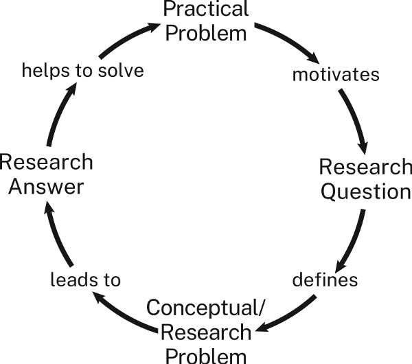

经验不足的研究人员有时会难以理解这些概念，因为经验丰富的研究人员通常用简略的语言谈论他们的工作。当被问及他们的研究方向时，他们常常会给出一些听起来像是我们之前提醒过你的那些宽泛主题的回答：比如*成人麻疹*、*艾米莉·狄金森的韵律，*或是怀俄明州麋鹿的*求偶*鸣叫。因此，初学者有时会误以为找到一个研究主题就等同于找到一个需要解决的问题。

Inexperienced researchers sometimes struggle with these notions because experienced researchers often talk about their work in shorthand. When asked what they are working on, they often answer with what sounds like one of those general topics we warned you about: *adult measles*, *Emily Dickinson’s prosody*, or *mating calls of Wyoming elk*. As a result, beginners sometimes think that having a topic to read about is the same as having a problem to solve.

### 2.1.4 实际问题和概念问题的共同点

### 2.1.4 What Practical and Conceptual Problems Have in Common

实际问题和概念问题都具有相同的两部分结构，但它们的条件和成本却有所不同。

Practical and conceptual problems have the same two-part structure, but they have different kinds of conditions and costs.

- ▪ 实际问题的状态可以是*任何*会给你或你的听众带来实际损失的情况。
- ▪ The condition of a practical problem can be *any* state of affairs that has a tangible cost for you or, better, for your audience.
- 然而，概念性问题的本质*总是*某种形式的不知道或不理解。
- ▪ The condition of a conceptual problem, however, is *always* some version of not knowing or not understanding something.

你可以通过完成以下三步句来识别概念性问题（参见1.3）：第一步是“*我正在学习/研究________这个主题*”。第二步，间接问句陈述了概念性问题的状态，即你不知道或不理解的内容：

You can identify the condition of a conceptual problem by completing that three-step sentence (see 1.3): The first step is *I am studying/working on the topic of* ________. In the second step, the indirect question states the condition of a conceptual problem, what you do not know or understand:

> 我正在研究二战时期“铆钉女工罗西”作为女权主义偶像的演变，因为我想了解**这个人物是如何以及为什么随着时间的推移获得了各种各样的含义。**

> I am studying the evolution of the World War II–era figure Rosie the Riveter as a feminist icon because I want to understand **how and why that figure has acquired a range of meanings over time.**

这就是为什么我们强调问题的价值：问题迫使你承认自己不了解或不理解但又渴望了解的事物。由于你的问题将指导你的研究，因此要特别注意问题的表述方式，它可能会如何引导你走向特定的方向，或者排除某些可能的答案或视角。例如，关于“铆钉女工罗西”的问题，其表述方式可能会让你忽略，甚至忽略罗西的形象是如何边缘化有色人种女性的。真正优秀的科研能够帮助我们和受众摆脱无知和偏见，但最难克服的偏见恰恰存在于我们提出的问题和难题本身之中。

That’s why we emphasize the value of questions: they force you to state what you don’t know or understand but want to. Since your problem will guide your research, be especially attentive to how its formulation might steer you in particular directions or exclude possible answers or perspectives. For example, the problem about Rosie the Riveter as it’s phrased might keep you from recognizing, or even looking into, how the original Rosie figure marginalizes women of color. Authentic research at its best elevates us and our audiences out of ignorance and bias, but the most difficult biases to resist are those embedded in our questions and problems themselves.

这两种问题带来的成本也不同。

The two kinds of problems also have two different kinds of costs.

- ▪实际问题的**代价**总是我们不喜欢的某种有形的东西或情况。
- ▪ The **cost** of a practical problem is always some tangible thing or situation we don’t like.

概念性问题不会产生这种切实的代价。事实上，我们将通过称概念性问题的代价为其*后果来强调这种区别*。

A conceptual problem does not have such a tangible cost. In fact, we’ll emphasize this difference by calling the cost of a conceptual problem its *consequence*.

- **概念性问题会导致**一种特殊的无知：正是由于缺乏理解，我们才无法理解其他更重要的事物。换句话说，因为我们没有回答一个问题，所以我们也无法回答另一个更重要的问题。
- ▪ The **consequence** of a conceptual problem is a particular kind of ignorance: it is a lack of understanding that keeps us from understanding something else even more significant. Put another way, because we haven’t answered one question, we can’t answer another that is more important.

研究人员选择研究项目往往只是出于好奇。事实上，我们大多数人最初对所研究的课题产生兴趣也是出于好奇。但要想让你的研究对他人有意义，你不能仅仅说“*我发现这个很有意思”，*而应该向他们展示解决你的问题如何帮助他们解决自身的问题。而做到这一点的方法就是解释你的问题所带来的后果。

Researchers often choose projects simply because they are curious. In fact, that’s how most of us first become interested in the subjects we study. But to make your research matter to others, you have to say more than *Here is something I find interesting*. You have to show them how solving your problem helps them solve theirs. You do that by explaining your problem’s consequence.

在我们的公式第三步中，您可以通过间接问句表达问题的后果：

You express a problem’s consequence in the indirect question in step 3 of our formula:

> 我正在研究二战时期“铆钉女工罗西”作为女权主义偶像的演变，因为我想了解这个人物是如何以及为什么随着时间的推移获得了各种各样的含义，从而理解**图像是如何被重新用于新的目的，以及它们如何具有许多观众没有意识到的排他性含义。**

> I am studying the evolution of the World War II–era figure Rosie the Riveter as a feminist icon because I want to find out how and why that figure has acquired a range of meanings over time to understand **how images can be repurposed to new ends and also have exclusionary meanings that many viewers didn’t recognize.**

这一切听起来可能令人困惑，但其实比看起来要简单得多。概念性问题的条件和结果这两个问题之间存在两种关联：

All of this may sound confusing, but it is simpler than it seems. The condition and the consequence of a conceptual problem are questions that relate to each other in two ways:

- ▪ 第一个问题（Q1）的答案有助于你回答第二个问题（Q2）。
- ▪ The answer to the first question (Q1) helps you answer the second (Q2).
- ▪ 第二个问题（Q2）的答案比第一个问题（Q1）的答案更重要。
- ▪ The answer to the second question (Q2) is more important than the answer to the first (Q1).

同样，研究问题的第一部分是你不知道但想要了解的东西。你可以将这种知识或理解上的不足表述为一个直接的问题：*过去五十年里，爱情电影发生了哪些变化？*或者，也可以表述为一个间接的问题：*我想了解过去五十年里爱情电影发生了哪些变化。*

Again, the first part of a research problem is something you don’t know but want to. You can phrase that gap in knowledge or understanding as a direct question: *How have romantic movies changed in the last fifty years?* Or as an indirect question: *I want to find out how romantic movies have changed in the last fifty years.*

现在想象一下有人问：*如果你回答不了这个问题怎么办？*你的回答是：说明*一些*比第一个问题的答案更重要的信息。例如：

Now imagine someone asking, *So what if you can’t answer that question?* You answer by stating *something else more important* that the answer to the first question helps you know. For example:

> 回答“过去五十年浪漫电影发生了哪些变化”这个问题<sub>（前提/第一个问题）有助于</sub> **我们回答一个更重要的问题：我们对浪漫爱情的文化描绘发生了哪些变化？** <sub>（结果/更重要的第二个问题）</sub>

> Answering the question of how romantic movies have changed in the last fifty years<sub>condition/first question</sub> **helps us answer a more important question: How have our cultural depictions of romantic love changed?**<sub>consequence/larger, more important second question</sub>

如果你认为回答第二个问题很重要，那么你就提出了一个值得探究的后果，如果你的听众也同意这一点，那么你就成功了。

If you think it’s important to answer that second question, you’ve stated a consequence that makes your problem worth pursuing, and if your audience agrees, you’re in business.

但如果你设想你的听众再次提出这样的问题：“*如果我们现在对浪漫爱情的描绘方式与过去是否有所不同，那又该如何呢？”*你必须提出一个更宏大的问题，你希望你的听众会认为这个问题意义重大：

But what if you imagine your audience again asking, *So what if I don’t know whether we now depict romantic love differently than we once did?* You have to pose a yet larger question that you hope your audience will think is significant:

> 回答“我们对浪漫爱情的描绘发生了怎样的变化”这个问题，**有助于**<sub>我们回答一个更重要的问题：我们的文化如何塑造年轻男女对婚姻和家庭的期望？</sub> <sub>（由此引申出一个更广泛、更重要的问题）</sub>

> Answering the question of how our depictions of romantic love have changed<sub>second question</sub> **helps us answer an even more important one: How does our culture shape the expectations of young men and women about marriage and families?**<sub>consequence/larger, more important question</sub>

如果你想象你的听众再次问“*那又怎样？”*，你可能会想，*找错听众了。*但如果你不得不面对这样的听众，你只能再试一次：*好吧，如果我们不回答这个问题，我们就无法……*

If you imagine your audience again asking, *So what?*, you might think, *Wrong audience.* But if that’s the audience you’re stuck with, you just have to try again: *Well, if we don’t answer that question, we can’t . . .*

学术界之外的人常常认为，学术专家们问的问题荒谬至极：*跳房子游戏是怎么起源的？*但他们却没意识到，研究人员之所以想要解答这类问题，是为了解答第二个更重要的问题。对于那些关心民间游戏如何影响儿童社会发展的人来说，未知带来的概念性后果恰恰证明了研究的必要性。*如果我们能够发现儿童民间游戏的起源，就能更好地理解游戏是如何帮助儿童进行社会化的；而且，在你问之前，我先解释一下，一旦我们了解了这一点，就能更好地理解……*

Those outside an academic field often think that its specialists ask ridiculously trivial questions: *How did hopscotch originate?* But they fail to realize that researchers want to answer a question like that so that they can answer a second, more important one. For those who care about the way folk games influence the social development of children, the conceptual consequences of not knowing justify the research. *If we can discover how children’s folk games originate, we can better understand how games socialize children, and, before you ask, once we know that, we can better understand . . .*

## 2.2 区分“纯粹”研究和“应用”研究

## 2.2 Distinguishing Between “Pure” and “Applied” Research

我们之前将真正的研究定义为由事先未知答案的问题所驱动的研究。我们可以区分两种类型。当研究探讨的是一个概念性问题，它不直接影响现实世界的任何实际情况，仅仅增进研究者群体的理解时，我们称之为*纯粹*研究。当研究探讨的概念性问题确实具有实际意义时*，我们称之为应用研究。你可以通过查看定义项目的三个步骤中的最后一个步骤来判断研究是纯粹研究还是应用研究。它指的是**“知道”还是*“做” ？

Earlier we described authentic research as research motivated by questions whose answers aren’t known in advance. We can distinguish two types. We call research *pure* when it addresses a conceptual problem that does not bear directly on any practical situation in the world, when it only improves the understanding of a community of researchers. We call research *applied* when it addresses a conceptual problem that does have practical consequences. You can tell whether research is pure or applied by looking at the last of the three steps defining your project. Does it refer to *knowing* or *doing*?

1. 1.**主题：**我正在研究宇宙某一区域的电磁辐射。
   1. 2.**问题：**因为我想知道天空中有多少个星系，
      1. 3.**意义：**为了帮助理解*宇宙是会永远膨胀还是最终坍缩成一个点。*
2. 1. **Topic:** I am studying the electromagnetic radiation in a section of the universe
   1. 2. **Question:** because I want to find out how many galaxies are in the sky,
      1. 3. **Significance:** in order to help *understand* whether the universe will expand forever or eventually collapse into a point.

那纯粹是研究，因为步骤 3 只涉及理解。

That is pure research because step 3 refers only to understanding.

这个问题需要应用研究，因为只有当天文学家*知道*如何解释大气畸变时，他们才能*做*他们想做的事情——更准确地测量光。

That problem calls for applied research because only when astronomers *know* how to account for atmospheric distortion can they *do* what they want to—measure light more accurately.

## 2.3 将研究与实际后果联系起来

## 2.3 Connecting Research to Practical Consequences

一些经验不足的研究者对纯粹的研究感到不安，因为概念性问题的后果——仅仅是不知道某些东西——太过抽象。由于他们尚未融入一个真正关心理解自身研究领域的群体，他们觉得自己的研究成果没什么用处。因此，他们试图将一些实际意义或结果强加给概念性问题，使其看起来更有价值：

Some inexperienced researchers are uneasy with pure research because the consequence of a conceptual problem—merely not knowing something—is so abstract. Since they are not yet part of a research community that cares deeply about understanding its part of the world, they feel that their findings aren’t good for much. So they try to cobble a practical consequence or significance on to a conceptual question to make it seem more significant:

1. 1.**研究主题：**我正在研究二战时期“铆钉女工罗西”作为女权主义偶像的演变历程。
   1. 2.**研究问题：**因为我想了解这个数字是如何以及为什么随着时间的推移而获得一系列含义的。
      1. 3.**潜在的实际意义：**帮助平面设计师设计更具包容性的政治海报。
2. 1. **Topic:** I am studying the evolution of the World War II–era figure Rosie the Riveter as a feminist icon
   1. 2. **Research Question:** because I want to find out how and why that figure has acquired a range of meanings over time
      1. 3. **Potential Practical Significance:** to help graphic artists design more inclusive political posters.

大多数人会认为步骤 2 和步骤 3 之间的联系有点牵强。

Most people would think that the link between steps 2 and 3 is a bit of a stretch.

要设计一个好的应用研究项目，你必须证明步骤 2 中间接问题的答案*能够合理地*帮助回答步骤 3 中的间接问题。请问自己以下问题：

To formulate a good applied research project, you have to show that the answer to the indirect question in step 2 *plausibly* helps answer the indirect question in step 3. Ask this question:

- （a）如果我的受众想要实现____________的目标[陈述你在步骤3中的目标]，
- (a) If my audience wants to achieve the goal of ____________ [state your objective from step 3],
- (b) 如果他们发现____________，他们会认为自己能做到吗？[请陈述你在第二步中提出的问题]
- (b) would they think that they could do it if they found out ____________? [state your question from step 2]

试试用这个测试方法来解答这道应用天文学问题：

Try that test on this applied astronomy problem:

- （a）如果我的听众想要利用地球上的望远镜的数据来更准确地测量电磁辐射的密度，
- (a) If my audience wants to use data from earthbound telescopes to measure more accurately the density of electromagnetic radiation,
- （b）如果他们知道大气层对测量结果的扭曲程度有多大，他们会认为自己可以做到吗？
- (b) would they think that they could if they knew how much the atmosphere distorts measurements?

答案似乎是*肯定的*。

The answer would seem to be *Yes*.

现在来试试“铆工罗西”的问题：

Now try the test on the Rosie the Riveter problem:

- （a）如果我的受众想要设计更好的政治竞选海报，
- (a) If my audience wants to design better political campaign posters,
- （b）如果他们知道“铆钉女工罗西”的形象是如何以及为什么随着时间的推移而获得各种含义的，他们会认为自己可以做到吗？
- (b) would they think they could if they knew how and why the figure of Rosie the Riveter acquired a range of meanings over time?

答案很可能是*否定的*。我们或许能看出一些联系，但这有点牵强。

The answer would probably be *No*. We may see a connection, but it’s a stretch.

如果你认为解决概念性问题的方法*可能*适用于实际问题，请将你的项目定位为纯研究，然后将应用部分作为*第四步**添加*：

If you think that the solution to your conceptual problem *might* apply to a practical one, formulate your project as pure research, then *add* your application as a *fourth* step:

1. 1.**研究主题：**我正在研究二战时期“铆钉女工罗西”作为女权主义偶像的演变历程。
   1. 2.**概念性问题：**因为我想了解这个数字是如何以及为什么随着时间的推移而获得一系列含义的。
      1. 3.**概念意义：**理解图像如何被重新用于新的目的，以及图像如何具有许多观众没有意识到的排他性含义。
         1. 4.**潜在的实际应用：**以便平面设计师能够设计更具包容性的政治海报。
2. 1. **Topic:** I am studying the evolution of the World War II–era figure Rosie the Riveter as a feminist icon
   1. 2. **Conceptual Question:** because I want to find out how and why that figure has acquired a range of meanings over time
      1. 3. **Conceptual Significance:** to understand how images can be repurposed to new ends and also have exclusionary meanings that many viewers didn’t recognize,
         1. 4. **Potential Practical Application:** so that graphic artists can design more inclusive political posters.

然而，在引言部分提出问题时，应将其描述为一个纯粹的概念性研究问题，其意义在于概念层面的推论。然后，等到结论部分再提出其实际应用。（更多内容请参见第14章。）

When you state your problem in your introduction, however, present it as a purely conceptual research problem whose significance is in its conceptual consequences. Then wait until your conclusion to suggest its practical application. (For more on this, see chapter 14.)

人文领域的大多数研究项目以及自然科学和社会科学领域的许多研究项目都与日常生活没有直接联系。但正如“*纯粹*”一词所暗示的那样，许多研究者认为这类研究比应用研究更受重视。他们相信，追求“为知识而求知”体现了人类的最高使命：求知若渴，并非为了金钱或权力，而是为了超越世俗的福祉，增进理解，丰富精神生活。

Most research projects in the humanities and many in the natural and social sciences have no direct application to daily life. But as the term *pure* suggests, many researchers value such research more than they do applied research. They believe that the pursuit of knowledge “for its own sake” reflects humanity’s highest calling: to know more, not for the sake of money or power, but for the transcendental good of greater understanding and a richer life of the mind.

正如您可能已经猜到的，我们致力于纯粹的研究。但对于应用研究而言，只要研究方法得当，不受恶意动机的影响，研究本身也是有益的。例如，潜在的盈利可能损害化学和生物科学领域纯粹研究和应用研究的完整性，因为它不仅会影响一些研究人员选择解决的问题，还会影响他们的解决方案：*告诉我们要寻找什么，我们就能找到！这种情况引发了伦理问题，我们将在*第17章“研究伦理”中探讨这些问题。

As you may have guessed, we are deeply committed to pure research, but also to applied—so long as the research is done well and is not corrupted by malign motives. For example, the potential for profit might compromise the integrity of both pure and applied research in the chemical and biological sciences because it can influence not only what problems some researchers choose to address but also their solutions: *Tell us what to look for, and we’ll provide it!* Such situations raise ethical questions that we touch on in chapter 17, “The Ethics of Research.”

## 2.4 寻找一个好的研究问题

## 2.4 Finding a Good Research Problem

伟大的研究者之所以能脱颖而出，是因为他们拥有卓越的才华、敏锐的洞察力，或者仅仅是凭借偶然的运气，发现一个问题，而这个问题的解决方式能让我们所有人以全新的视角看待世界。当我们偶然遇到一个好问题，或者问题主动找上门来时，我们很容易就能识别出来。但研究者常常在不了解真正问题是什么的情况下就开始一个项目。有时，他们只是希望更清晰地定义一个难题。事实上，那些发现新问题或阐明旧问题的人，往往比那些解决已定义问题的人对所在领域做出更大的贡献。有些研究者甚至因为*推翻了他们原本想要证明的*看似合理的假设而名声大噪。

What distinguishes great researchers from the rest of us is the brilliance, knack, or just dumb luck of stumbling over a problem whose solution makes all of us see the world in a new way. It’s easy to recognize a good problem when we bump into it, or it bumps into us. But researchers often begin a project without knowing what their real problem is. Sometimes they hope just to define a puzzle more clearly. Indeed, those who find a new problem or clarify an old one often make a bigger contribution to their field than those who solve a problem already defined. Some researchers have even won fame for *disproving* a plausible hypothesis that they had set out to prove.

所以，如果在项目初期你无法完全明确问题所在，也不要气馁。我们当中很少有人能做到这一点。但及早思考问题可以为你节省后续大量的工作时间（或许还能避免临近尾声时的慌乱）。它还能让你进入一种对后续工作至关重要的思维状态。以下是一些帮助你识别和完善好问题的方法。

So don’t be discouraged if you can’t formulate your problem fully at the outset of your project. Few of us can. But thinking about it early will save you hours of work along the way (and perhaps panic toward the end). It also gets you into a frame of mind crucial to advanced work. Here are some things you can do to identify and refine a good problem.

### 2.4.1 寻求帮助

### 2.4.1 Ask for Help

像经验丰富的研究人员那样做：与同事、老师、同学、亲戚、朋友、邻居——任何可能感兴趣的人交谈。为什么有人会想要你问题的答案？他们会用这个答案做什么？答案又会引发哪些新的问题？

Do what experienced researchers do: talk to colleagues, teachers, classmates, relatives, friends, neighbors—anyone who might be interested. Why would anyone want an answer to your question? What would they do with it? What new questions might an answer raise?

如果你可以自由地研究任何问题，那就找一个大问题的一部分，哪怕只是其中的一小部分。虽然你可能无法解决整个大问题，但你所研究的这部分也会对整个问题产生重要影响。（你还能借此机会了解你所在领域的问题，这可不是什么小好处。）如果你是学生，可以问问老师他们在研究什么，以及你是否可以参与其中的一部分。不要让他们的建议左右你的决定。你的研究存在局限性。没有什么比学生仅仅按照老师的建议去做，而没有做任何额外的工作更让老师感到沮丧的了。*老师*希望你用他们的建议来*启发*你的思考，而不是*止步*于此。没有什么比你运用他们的建议发现他们意想不到的东西更让老师高兴的了。

If you are free to work on any problem, look for a small one that is part of a bigger one. Though you won’t solve the big one, your small piece of it will inherit some of its larger significance. (You will also educate yourself about the problems of your field, no small benefit.) If you are a student, ask your teachers what they are working on and whether you can work on part of it. Don’t let their suggestions define the limits of your research. Nothing discourages a teacher more than a student who does *exactly* what is suggested *and no more*. Teachers want you to use their suggestions to *start* your thinking, not *end* it. Nothing makes teachers happier than when you use their suggestions to find something they never expected.

### 2.4.2 阅读过程中寻找问题

### 2.4.2 Look for Problems as You Read

你也可以在资料来源中发现研究问题。你在这些资料中发现了哪些矛盾、不一致或不完整的解释？不妨先假设其他人也会或应该有同样的感受。许多研究项目都始于与资料来源作者的一场假想对话：“*等等，你忽略了……”。*但在你着手纠正某个漏洞或误解之前，务必确认它是真实存在的，而不仅仅是你自己的误读。无数的研究论文都反驳过一些根本没人提出过的观点。（在4.3节中，我们列举了作者们为了发现资料来源中的问题而常用的几种“方法”，这些方法都类似于“*资料来源认为X，但我认为Y”*。）

You can also find research problems in your sources. Where in them do you see contradictions, inconsistencies, incomplete explanations? Tentatively assume that others would or should feel the same. Many research projects begin with an imaginary conversation with the author of a source: *Wait a minute, you’re ignoring . . .* But before you set out to correct a gap or misunderstanding, be sure it’s real, not just your own misreading. Countless research papers have refuted a point that no one ever made. (In 4.3 we list several common “moves” that writers make to find a problem in a source, variations on *Source thinks X, but I think Y.*)

一旦你认为自己发现了一个真正的谜题或错误，不要仅仅指出来就完事。如果某个资料来源说的是X，而你认为的是Y，那么你可能遇到了研究问题，但前提是你能证明那些认为X的人也误解了某些更深层次的问题。

Once you think you’ve found a real puzzle or error, do more than just point to it. If a source says X and you think Y, you may have a research problem, but only if you can show that those who think X misunderstand some larger issue as well.

最后，仔细阅读资料的最后几页。许多研究者会在那里提出更多需要解答的问题。以下段落的作者刚刚解释完19世纪俄罗斯农民的生活如何影响他们作为士兵的表现：

Finally, read the last few pages of your sources closely. That’s where many researchers suggest more questions that need answers. The author of the following paragraph had just finished explaining how the life of nineteenth-century Russian peasants influenced their performance as soldiers:

> 正如士兵的和平时期经历影响了他们在战场上的表现一样，军官的经历也必然影响了他们在战场上的表现。事实上，日俄战争后，一些评论家将俄军的战败归咎于军官在日常事务中养成的习惯。无论如何，为了了解沙皇时期军官在和平时期和战争时期的服役习惯，*我们需要对军官队伍进行结构性分析——或者说，一种人类学分析——就像本文对士兵所做的那样。* [重点为原文所有]

> And just as the soldier’s peacetime experience influenced his battlefield performance, so must the experience of the officer corps have influenced theirs. Indeed, a few commentators after the Russo-Japanese War blamed the Russian defeat on habits acquired by officers in the course of their economic chores. In any event, to appreciate the service habits of Tsarist officers in peace and war, *we need a structural—if you will, an anthropological—analysis of the officer corps like that offered here for enlisted personnel.* [our emphasis]

最后一句话引出了一个新问题，等着你去解决。

That last sentence offers a new problem waiting for you to tackle.

### 2.4.3 审视你自己的结论

### 2.4.3 Look at Your Own Conclusion

批判性阅读也能帮助你在自己的草稿中发现好的研究问题。我们往往在写作的最后几页思路最为清晰，因为正是在这段时间里，我们会提出一些起初并未预料到的观点。如果在早期草稿中你突然想到一个意料之外的观点，不妨问问自己，它可能回答了什么问题。这听起来或许有些矛盾，但你可能已经回答了一个你尚未提出的问题，从而解决了一个你尚未提出的难题。你的任务就是找出这个难题究竟是什么。

Critical reading can also help you discover a good research problem in your own drafts. We often do our best thinking in the last few pages that we write because it is there that we formulate claims we did not anticipate when we started. If in an early draft you arrive at an unanticipated claim, ask yourself what question it might answer. Paradoxical as it might seem, you may have answered a question that you have not yet asked and thereby solved a problem that you have not yet posed. Your task is to figure out what that problem might be.

## 2.5 学习如何处理问题

## 2.5 Learning to Work with Problems

经验丰富的研究人员渴望发现新的问题并加以解决。更大的梦想是解决一个甚至无人知晓的问题。然而，只有当其他人认为（或被说服）这个问题需要解决时，这个新问题才具有价值。因此，经验丰富的研究人员在面对一个问题时首先应该问的不是“*我能解决它吗？”*，而是*“其他人会认为它需要解决吗？”*

Experienced researchers dream of finding new problems to solve. A still bigger dream is to solve a problem that no one even knew they had. But that new problem isn’t worth much until others think (or can be persuaded) that it needs solving. So the first question an experienced researcher should ask about a problem is not *Can I solve it?* but *Will others think it should be solved?*

没人指望你第一次就能做到所有这些。但你应该开始培养一些思维习惯，为那一刻做好准备。研究不仅仅是收集和记录事实。试着提出一个*你*认为值得解答的问题，这样将来你就能找到*别人*认为值得解决的问题。在你做到这一点之前，你可能会面临研究者最不愿遇到的回应——不是“我*不同意”* ，而是“我*不在乎”（*参见 I.4.3、6.2 和 9.1）。

No one expects you to do all that the first time out. But you should begin to develop mental habits that will prepare you for that moment. Research is more than just accumulating and reporting facts. Try to formulate a question that *you* think is worth answering, so that down the road, you’ll know how to find a problem that *others* think is worth solving. Until you can do that, you risk the worst response a researcher can get—not *I don’t agree* but *I don’t care* (see I.4.3, 6.2, and 9.1).

如今，所有这些关于学术研究的空谈似乎与某些人所谓的“现实世界”脱节。但在商业和政府、法律和医学、政治和国际外交领域，没有什么技能比发现问题并能清晰阐述问题的能力更重要，这种能力不仅能让其他人关心问题，还能让他们相信问题可以解决，尤其是由你来解决。如果你能在拜占庭陶器课堂上做到这一点，那么你也能在商业街或华尔街的办公室里做到这一点，甚至在自家厨房的餐桌上通过视频会议做到这一点。

By now, all this airy talk about academic research may seem disconnected from what some call the “real world.” But in business and government, in law and medicine, in politics and international diplomacy, no skill is valued more highly than the ability to recognize a problem, then to articulate it in a way that convinces others both to care about it and to believe it can be solved, especially by you. If you can do that in a class on Byzantine pottery, you can do it in an office on Main Street or Wall Street, or in a video conference from your kitchen table.

▶ 小贴士：如何利用经验不足的机会

▶ Quick Tip: Making an Opportunity of Inexperience

当我们开始涉足一个全新的领域，面对我们并不完全了解的价值观、关注点、思维方式和论证方法时，都会感到焦虑。事实上，即使是我们这些作者，在开始撰写关于新主题的新项目时，也仍然会经历这种新手的焦虑。这种感觉有时难以避免，但有一些方法可以帮助我们应对：

We all feel anxious when we start work in a new field whose values, concerns, and ways of thinking and arguing we don’t entirely understand. In fact, we authors still experience that newcomer’s anxiety when we begin new kinds of projects on new topics. You can’t avoid experiencing that feeling at times, but there are ways to manage it:

- 要 *知道，不确定感和焦虑感是自然且不可避免的。*这些感觉并不代表能力不足，而只是缺乏经验。
- ▪ *Know that uncertainty and anxiety are natural and inevitable.* Those feelings don’t signal incompetence, only inexperience.
- ▪ *通过边写边研究来掌控你的主题。*坚持写日记，反思你的进展。这种写作方式不仅能帮助你理解阅读内容，还能激发你的思考。越早开始写作，哪怕只是粗略的草稿，就越容易面对令人望而生畏的初稿。
- ▪ *Get control over your topic by writing about it along the way.* Keep a journal in which you reflect on your progress. This kind of writing not only helps you understand what you read but stimulates your thinking about it. The more you write early on, no matter how sketchily, the easier it will be to face that intimidating first draft.
- ▪ *对信息来源做出回应，而不仅仅是堆砌它们。*当你发现有用的信息来源时，不要只是拍照、截图或将其留在浏览器标签页中。这样做虽然简单，但并不能促进你的思考。此外，还要撰写摘要或评论。列出该信息来源引发你思考的任何问题。
- ▪ *Respond to your sources; don’t just accumulate them.* When you discover a useful source, don’t just snap a photo of it, grab a screenshot of it, or leave it open in a browser tab. That’s easy, but it doesn’t advance your thinking. In addition, write a summary or critique. List any questions that source raises in your mind.
- 将 *任务分解成易于管理的小步骤，并明白这些步骤是相辅相成的。*一旦你提出了一个好问题，你就能更有效地撰写和修改初稿。你越是预先设想如何撰写和修改初稿，你的写作效率就越高。
- ▪ *Break the task into manageable steps and know that they are mutually supportive.* Once you formulate a good question, you’ll draft and revise more effectively. The more you anticipate how you will write and revise a first draft, the more effectively you will produce it.
- 如果 *你是一名学生，请相信你的老师会理解你的困难。*他们希望你成功，你可以期待他们的帮助。你也可以向图书馆员或学校的写作中心寻求帮助。
- ▪ *If you are a student, count on your teachers to understand your struggles.* They want you to succeed, and you can expect their help. You can also turn to librarians or your campus writing center.
- ▪ *设定切合实际的目标。*即使听众不认同你的观点，但如果他们认可你的论证有力，那么你就做了一件意义非凡的事情。
- ▪ *Set realistic goals.* You do something significant when, even if your audience doesn’t agree with your claim, they recognize that you argued it well.
- 最重要的是 *，要认识到这种挣扎的本质——它是一次学习经历。*为了应对焦虑并克服所有初学者都会遇到的困难，要学习成功研究人员的做法，尤其是在感到沮丧的时候：回顾你的计划和已撰写的内容，然后继续前进。成功的研究人员知道，虽然没有绝对的把握，但大多数精心构思的研究项目最终都会取得不错的成果。或许只是“还不错——考虑到种种因素”，但很可能远不止于此。
- ▪ *Most important, recognize the struggle for what it is—a learning experience.* To manage the anxiety and overcome the struggles that all beginners face, do what successful researchers do, especially when discouraged: review your plan and what you’ve written, then press on. Successful researchers know that while there are no sure things, most well-conceived research projects will turn out OK. Perhaps only “OK—considering,” but probably a lot better than that.

# 第二部分

# Part II

# 资源和资料

# Sources and Resources

# 序幕

# Prologue

# 资料来源和权威研究

# Sources and Authentic Research

研究的形式多种多样，取决于研究领域和提出的问题。一些研究者在实验室进行实验；一些观察自然界或人类行为；一些通过调查或访谈收集数据；还有一些分析或解读文本、听觉、视觉或实物资料，等等。接下来的两章，我们将重点讨论基于资料的研究。之所以如此，是因为运用资料是最常见的研究形式，通常也是我们大多数人最先学习的研究方法。第三章，我们将重点讨论如何查找和评估资料的相关性和可靠性。第四章，我们将重点讨论如何准备在论证中使用这些资料。虽然我们将这些步骤视为独立的步骤，但实际上它们是相互交织的。在真正的研究中，你不会先找到所有资料，然后再阅读并做笔记。相反，一旦你找到一个好的资料，它就会引导你找到其他资料。你会继续阅读和探索，并运用在此过程中获得的知识来完善你的研究，最终找到问题的答案。这种寻找、评估和利用信息来源的循环方法是所有真实研究的特征。

Research can take many forms, depending on the field of study and the questions that you ask. Some researchers do experiments in laboratories; some observe the natural world or human behavior; some collect data from people through surveys or interviews; some analyze or interpret textual, aural, visual, or material sources, among other methods. In the next two chapters, we focus on research based on sources. We do so because working with sources is the most common form of research and typically the first kind most of us learn. In chapter 3, we focus on locating and evaluating sources for their relevance and reliability. In chapter 4, we focus on preparing to use these sources in arguments. While we treat these as separate steps, in reality they are intertwined. In authentic research, you don’t first find all your sources, then read and take notes on them. Rather, once you find one good source, it will lead you to others. You read and explore further using the knowledge you gain along the way to refine your inquiry and inform an answer to your question. This cyclic approach to locating, evaluating, and engaging sources is characteristic of all authentic research.

# 3 寻找和评估信息来源

# 3 Finding and Evaluating Sources

如果您是研究新手，并且预计大部分资料将来自图书馆或网络，本章将帮助您制定研究计划。如果您经验丰富，可以直接跳到下一章。

If you are a new researcher and expect to find most of your sources in your library or online, this chapter will help you develop a plan for your research. If you are more experienced, you might skip to the next chapter.

初学者往往认为研究就是寻找信息来充实论文，尤其是那些他们认为*能够支持*自己论点的信息。这种研究观是错误的。它假定所有证据都是一样的，并且认为研究就是按照老师布置的作业要求找到足够多的资料来源。当然，在某些情况下，老师会要求学生使用最少数量的资料来源，或者只使用*学术*资料，或者避免使用维基百科。为了规划你的研究项目，你必须了解哪些类型的材料可以作为资料来源，以及如何在你的论证中使用它们。

Beginning researchers often think of research as just finding information to put into their papers, especially information they believe *backs up* their arguments. This view of research is wrong. It assumes that all evidence is the same and that research involves finding enough sources as specified by an assignment from a teacher. In some cases, of course, students are told to use a minimum number of sources or to use only *scholarly* sources or to avoid Wikipedia as a source. To plan your research project, you must understand what kinds of materials serve as sources and how to use them in your argument.

## 3.1 理解三种信息来源

## 3.1 Understanding Three Types of Sources

传统上，资料来源分为三类：一手资料、二手资料和三手资料。它们的界限并不清晰，但了解这些分类有助于你规划研究。它们的主要区别在于研究者如何使用它们。

Sources are conventionally categorized into three kinds: primary, secondary, and tertiary. Their boundaries are fuzzy, but knowing these categories can help you plan your research. They differ primarily in the uses to which a researcher puts them.

### 3.1.1 证据的主要来源

### 3.1.1 Primary Sources for Evidence

原始资料是指提供“原始数据”或证据的“原始材料”，您将使用这些材料来发展和检验您的假设或主张，并最终支持您的论证理由。不同领域的原始资料定义差异很大。在历史学中，原始资料是指直接来自史料或文献的文物。你研究的时期或事件可以是信件、日记、物品、地图，甚至是衣物。在文学或哲学领域，你的主要原始资料通常是你正在分析的文本（例如，莎士比亚的《*麦克白》*或汉娜·阿伦特的《*人的境况》） ，你的数据就是文本上的文字。在艺术批评中，你的原始资料是你所解读的艺术作品。在社会科学领域，例如社会学或政治学，人口普查或调查数据也属于原始资料，通过访谈、田野调查（民族志观察）或实验获得的数据也属于原始资料。在自然科学领域，原创研究报告有时也被视为原始资料（尽管科学家本身很少使用这个术语）。*

Primary sources are “original” materials that provide you with the “raw data” or evidence you will use to develop and test your hypothesis or claim and ultimately to support the reasons in your argument. What counts as a primary source varies significantly by field. In history, primary sources are artifacts or documents that come directly from the period or event you are studying: letters, diaries, objects, maps, even clothing. In literature or philosophy, your main primary source is usually the text (e.g., Shakespeare’s *Macbeth* or Hannah Arendt’s *The Human Condition*) you are analyzing, and your data are the words on the page. In arts criticism, your primary source would be the work of art you are interpreting. In social sciences, such as sociology or political science, census or survey data would also count as primary, as could data obtained through interviews, fieldwork (ethnographic observation), or experiments. In the natural sciences, reports of original research are sometimes characterized as primary sources (although scientists themselves rarely use that term).

### 3.1.2 向其他研究者学习的二手资料

### 3.1.2 Secondary Sources for Learning from Other Researchers

二手资料是指基于一手资料撰写，面向学术或专业读者的书籍、文章或报告。某一领域的二手资料总和有时被称为该领域的*文献。*最佳的二手资料包括来自知名大学出版社的书籍以及经过同行*评审的文章或报告，这*意味着它们在出版前已经过该领域专家的审查。研究人员阅读二手资料是为了了解各自领域的最新进展，并以此激发自身的思考。构建新研究问题的标准方法是挑战或拓展他人已发表在二手资料中的结论或方法。二手资料还包括收录该领域学者文章的专业百科全书和词典。二手资料过去主要通过高校图书馆获取，但现在也可以通过在线目录和数据库获取，例如 EBSCOhost 和 Google Scholar。

Secondary sources are books, articles, or reports that are based on primary sources and are intended for scholarly or professional audiences. The body of secondary sources in a field is sometimes called that field’s *literature*. The best secondary sources are books from reputable university presses and articles or reports that have been *peer-reviewed*, meaning that they were vetted by experts in the field before they were published. Researchers read secondary sources to keep up with developments in their fields and, in this way, to stimulate their own thinking. The standard way of framing new research problems is to challenge or build on the conclusions or methods of others, as presented in secondary sources they have written. Secondary sources also include specialized encyclopedias and dictionaries that offer essays by scholars in a field. Secondary sources were once available mainly through college and university libraries, but they are also available through online catalogs and databases, including EBSCOhost and Google Scholar.

你可以出于以下三个主要目的使用二手资料：

You can use secondary sources for three main purposes:

1. 1.**了解其他人对你研究主题的论述。**二手资料是了解其他研究者对你研究主题的看法以及他们认为哪些问题重要的最佳途径。（不仅要关注他们提出的研究问题，还要关注他们提出的任何其他问题。）你或许可以借鉴其中某个问题来构建你的研究问题。
2. 1. **To learn what others have written about your topic.** Secondary sources are the best way to learn what other researchers have said about your topic as well as what kinds of questions they think are important. (Pay attention not only to the research questions they address but also to any additional questions they pose.) You may be able to model your question on one of these.
3. 2.**寻找其他观点。**初学者有时会认为，如果提及与自己观点相悖的想法，就会削弱自己的论证。但事实恰恰相反：当你承认对立观点时，不仅表明你已经考虑过这些观点，也表明你能够回应它们（参见第九章）。只有当你设想并回应读者可能提出的问题和异议时，你的研究才算完整。你可以在二手资料中找到这些。他们提出了哪些与你的观点不同的替代方案？他们引用了哪些你必须承认的证据？更重要的是，你可以利用他人的论点来检验和完善自己的观点。只有了解一个理性的人为何会持有不同观点，你才能真正理解自己的想法。因此，在寻找资料时，不仅要寻找支持你观点的资料，还要寻找挑战你观点的资料。
4. 2. **To find other points of view.** Beginning researchers sometimes believe they will weaken their case if they mention ideas that contradict their own. The opposite is actually true: when you acknowledge opposing views, you show your audience not only that you have considered those views but also that you can respond to them (see chapter 9). Your research will be complete only when you imagine and respond to your audience’s predictable questions and disagreements. You can find those in secondary sources. What alternatives to your ideas do they offer? What evidence do they cite that you must acknowledge? More important, you can use the arguments of others to test and improve your own. You cannot understand what you think until you know why a reasonable person might think differently. So as you search for sources, look not only for those that support your views but also for those that challenge them.
5. 3.**寻找研究和写作的范例。**你可以利用二手资料，不仅了解其他人对你的主题写了些什么，还要了解他们是*如何*写作的。如果你的大多数资料都使用了标题、图表和大量的要点，那么你可以考虑也这样做；如果你的资料从未使用过这些，你可能就不应该这样做。注意一些细节，例如语言（专业术语还是通俗易懂？）、段落（长段落还是短段落？）以及他们如何使用其他资料（引用还是转述？）。特别注意他们大多使用的证据类型以及他们很少或从未使用的证据类型。你还可以将二手资料作为自己论证的范例。你不能直接照搬资料中的具体论点和理由，但你可以在自己的论证中使用类似的推理方式，甚至可以采用相同的结构。因此，如果你遇到一篇并非完全针对你的主题，但却以类似方式论述的资料，不妨快速浏览一下，看看你能从中学习到哪些论证方法。 （如果您只是引用该来源的逻辑，则无需注明出处；但您可以引用该来源以增强您自身论点的说服力。）
6. 3. **To find models for your own research and writing.** You can use secondary sources to find out not just what others have written about your topic but also *how* they have written about it. If most of your sources use headings, charts, and lots of bullet points, then you might consider doing the same; if your sources never use them, you probably shouldn’t. Notice things like the language (technical or broadly accessible?), paragraphs (long or short?), and how they use other sources (quotation or paraphrase?). Pay special attention to the kinds of evidence most of them use and the kinds of evidence they rarely or never use. You can also use secondary sources as models for your own argument. You cannot reuse a source’s specific claims and reasons, but you can use the same kind of reasoning in your own argument, perhaps even following the same organization. So if you come across a source that’s not precisely on your topic but treats one like it, skim it to see what you can learn about how to argue your case. (You don’t have to cite that source if you use only its logic, but you may cite it to give your own more authority.)

### 3.1.3 导论性概述的第三手资料

### 3.1.3 Tertiary Sources for Introductory Overviews

三级文献是指面向普通读者，综合二级文献内容的书籍和文章。它们包括教科书、百科全书（包括维基百科）条目以及面向大众的出版物文章。*例如，像《今日心理学》*这样的媒体，甚至是一些教育类的YouTube视频，都是不错的参考资料。在研究初期，你可以利用三手资料来大致了解你的研究主题。但如果你要进行学术论证，就应该依赖二手资料，因为这些资料构成了你想要参与的学术讨论。如果在学术论证中引用三手资料，你会显得自己要么是新手，要么是局外人，很多读者不会认真对待你或你的论点。

Tertiary sources are books and articles that synthesize secondary sources for general readers. They include textbooks, articles in encyclopedias (including Wikipedia), articles in publications for broad audiences like *Psychology Today*, or even some educational YouTube videos. In the early stages of research, you can use tertiary sources to get a broad overview of your topic. But if you are making a scholarly argument, you should rely on secondary sources because these make up the conversation in which you are seeking to participate. If you cite tertiary sources in a scholarly argument, you will mark yourself as either a novice or an outsider, and many readers won’t take you or your argument seriously.

这种说法或许听起来不太公平，但并非如此。三手资料并非一定错误——事实上，其中许多出自杰出学者之手——但它们确实存在局限性。由于三手资料面向的是对相关主题不熟悉的广大读者，因此它们有时会过度简化其研究基础，而且容易过时。但如果您牢记这些局限性，三手资料仍然可以成为宝贵的资源：它们可以为您介绍一些您不熟悉的主题，而且如果它们附有参考文献，有时还能引导您找到有价值的二手资料。

This response may seem unfair, but it’s not. Tertiary sources aren’t necessarily wrong—many are in fact written by distinguished scholars—but they are limited. Because they are intended for broad audiences who are unfamiliar with the topics they address, tertiary sources can sometimes oversimplify the research on which they are based, and they are susceptible to becoming outdated. But if you keep these limitations in mind, tertiary sources can be valuable resources: they can inform you about topics that are new to you, and if they have bibliographies, they can sometimes lead you to valuable secondary sources.

### 3.1.4 区分一手资料、二手资料和三手资料

### 3.1.4 Differentiating Primary, Secondary, and Tertiary Sources

研究人员并非一直将资料分为这三类。一手资料和二手资料的区分起源于19世纪的历史学家，之后扩展到其他领域。三手资料这一类别是后来才加入的。虽然现在这套分类方法已成为学生学习资料分类的标准方式，但它对某些学科的适用性高于其他学科。它非常适用于历史学，因为历史学的一手资料是指与特定历史事件或时期直接相关的材料；也适用于批评学，因为批评学的一手资料是指你所解读的艺术、音乐或文学作品的原作。但对于数学、化学或护理学等学科来说，它的适用性就没那么高了。

Researchers haven’t always divided their sources into these three categories. The distinction between primary and secondary sources originated with historians in the nineteenth century and then spread to other fields. The category of tertiary sources was added later. Although this scheme is now the standard way that students are taught to classify sources, it fits some disciplines better than others. It works very well for history, in which primary sources are materials directly connected to a historical event or moment, and for criticism, in which primary sources are the original works of art, music, or literature that you are interpreting. But it works less well for, say, mathematics, chemistry, or nursing.

It is also important to understand that the classifications of primary, secondary, and tertiary are not absolute but relative to a researcher’s project. In most instances, an article in a scholarly journal would be considered a secondary source. But it would become a primary source if your research problem concerned its author or the field itself, for example, if you were writing a biography of the anthropologist Margaret Mead. Likewise, T. S. Eliot’s essay “Hamlet and His Problems” would be a primary source if you were studying Eliot but a secondary source if you were studying Shakespeare. An encyclopedia article would usually be considered a tertiary source, but it would become a primary source if you were studying the way that encyclopedias deal with gender issues. A TED Talk on election campaigns might be a tertiary source in political science but a primary source in media studies. Change your focus and you change the classification of your sources.

如果这让你感到困惑，其实不必如此。记住，这些分类只是达到目的的手段。最终，重要的不是你如何*称呼*你的资料来源，而是你如何有效地*运用*它们来解决你的研究问题、发展新思路并提出引人入胜的论点。在下一章中，我们将更详细地讨论如何在写作中使用资料来源。

If this is confusing, it need not be. Remember that these classifications are just a means to an end. The important thing, ultimately, is not what you *call* your sources but how well you *use* them to address your research problems, develop new ideas, and make interesting arguments. In the next chapter, we will talk more about how you can use sources in your writing.

## 3.2 充分利用图书馆

## 3.2 Making the Most of the Library

即使有了互联网，图书馆也无可替代。你不仅可以利用图书馆查找特定主题的资料，还可以探索和深化你想要研究的主题和问题。无论你是亲自前往（我们强烈推荐），还是在线访问，图书馆都是不可或缺的研究工具。鉴于如今网络上信息浩如烟海，你或许会认为，除了高度专业化的研究之外，图书馆已不再必要。然而，事实恰恰相反。信息*触手可及的*今天，图书馆在研究中的重要性比以往任何时候都更加突出。图书馆不仅让我们能够获取信息，还能确保信息的可靠性。即使你的公共图书馆或大学图书馆规模相对较小，它也能为你打开通往更广泛资源的*门户*——研究指南、参考书、在线数据库和内容——从而拓展图书馆的服务范围。当然，要想充分利用这些资源，你必须学会如何使用图书馆。

Even with the internet, there is no substitute for the library. You can use the library not just to find sources on a topic but to explore and refine topics and research questions you might want to pursue. Whether you visit in person, which we highly recommend, or virtually, the library is an indispensable tool for research. Given the volume of information now available online, you might think libraries are no longer necessary except, perhaps, for highly specialized research. However, the opposite is true. With *so much* information at our fingertips, libraries are more essential than ever in doing research. Libraries not only let us access information but also ensure that our sources are reliable. Even if your public or academic library is comparatively small, it serves as a *portal* to a much broader range of resources—research guides, reference works, and online databases and content—that extends the library’s reach. Of course, to benefit from these resources, you must learn to navigate the library.

### 3.2.1 规划您的图书馆检索

### 3.2.1 Planning Your Library Search

在使用资料来源之前，您必须先找到并评估它们。一些最终会成为资料来源的材料可能就存放在您的图书馆里；而另一些则可能在其他地方，例如网上或其他场所。在其他图书馆。因此，要想充分利用图书馆提供的资源，您必须*提前规划*好检索路线。幸运的是，这正是图书馆及其图书管理员最能发挥作用的地方。

Before you can use sources, you must first find and evaluate them. Some materials that will eventually serve as sources will be physically located in your library; others are likely elsewhere, whether online or at another library. To take advantage of what libraries have to offer, then, you must *plan* your search. Fortunately, this is where libraries—and librarians—are most useful.

一开始，如何着手查找资料可能会让人不知所措。有了研究主题或问题后，人们很容易直接在图书馆的搜索引擎中输入几个关键词，看看能搜到什么结果。我们也会这样做，但我们也知道，图书馆提供了更系统、更高效的方法来发现有用且可靠的资源。

Knowing where to begin a search can be overwhelming at first. With a topic or a research question in hand, it is tempting simply to enter a few terms in your library’s search engine and see what comes up. We do this too, but we also know that the library offers more systematic and productive methods for discovering useful and credible sources.

咨询图书馆员。或许我们能提供的最佳建议就是依靠图书馆员的研究专长。无论是普通参考咨询馆员，还是（在规模较大的图书馆中）学科专家，都能帮助您优化检索参数，并指导您找到针对特定研究问题的合适工具。他们可以帮助您使用馆藏目录查找本馆或其他图书馆的馆藏资料（以及可通过馆际互借获取的资料）。这些图书馆员通常还会编写研究指南，列出特定领域的参考书目和在线数据库。

Ask a Librarian. Perhaps the best advice we can offer is to rely on the research expertise of librarians. Both general reference librarians and (in larger libraries) subject-area specialists can help you refine your search parameters and direct you to the right tools for your specific research question. They can help you use the catalog to locate materials held by your library or by other libraries (and obtainable through interlibrary loan). These same librarians typically design research guides that identify reference works and online databases for specific fields.

别害羞。图书馆员乐于帮助各个层次、各个阶段的研究人员。他们可以帮助您明确研究问题、制定检索词，并整理检索结果，确保您没有遗漏任何有价值的信息。唯一令人尴尬的问题是您*应该问却没问的问题。当然，提前做好准备对繁忙的图书馆员来说是有益的。如果您已经准备好一个完善的研究问题，图书馆员就能更好地为您提供建议。您可以参考*第一章中的三步评估标准来描述您的项目：

And don’t be shy. Librarians love to assist researchers of all levels and at all stages of the research process. They can help you formulate your research question, develop search terms, and inventory your results to ensure you haven’t overlooked something of value. The only embarrassing question is the one you *failed to ask* but should have. Of course, it pays to meet busy librarians halfway by preparing in advance. If you have a well-developed research question ready to share, your librarian will be able to give you better advice. You might describe your project using the three-step rubric from chapter 1:

1. 1. 我正在研究20世纪80年代的教育政策。
   1. 2. 了解中西部地区的学校董事会如何处理种族融合问题
      1. 3. 因为我想了解种族关系中的地区差异。
2. 1. I am working on educational policy in the 1980s
   1. 2. to find out how school boards in the Midwest dealt with desegregation
      1. 3. because I want to understand regional differences in race relations.

查阅参考资料。如果您对某个主题已经非常了解，您可能也知道如何找到相关资料。但如果您对这个主题还不熟悉，那就需要参考其他资料了。对于某个主题，切勿急于直接查阅你认为相关的原始资料或二手资料。这种方法既不可靠又难以预测，而且可能也节省不了你的时间。更有效的策略是让参考书引导你的检索工作。由专家编纂的综合性参考书，例如《*不列颠百科全书》，以及*更专业的参考书，例如《哲学*百科全书》* ，都能为你提供大致的概览，让你更容易理解你的资料在整体框架中的位置。此外，参考书通常包含引文或书目，这些引文或书目可以引导你找到那些你可能忽略的资料。

Consult Reference Works. If you already know a lot about your topic, you probably also know how to find sources on it. But if you are new to a topic, resist the temptation to go straight to primary or secondary sources that strike you as relevant. This approach is unreliable and unpredictable and probably won’t save you any time. A more successful strategy is to allow reference works to shape your search efforts. Compiled by experts, both general reference works such as the *Encyclopaedia Britannica* and more specialized works such as the *Encyclopedia of Philosophy* will give you the lay of the land, so that later it will be easier to see how your sources fit within the bigger picture. In addition, reference works often include citations or bibliographies that can lead you to sources you might otherwise overlook.

在研究初期，书目资料尤为重要，其中许多都提供了关于某一主题的重要文章或书籍的摘要。寻找带有注释的书目或年度文献综述，这些资料通常会总结近期出版的书籍或文章，因为它们往往能为你的研究提供有价值的线索。

Especially valuable at early stages of research are bibliographic works, many of which provide abstracts summarizing significant articles or books on a topic. Look for annotated bibliographies or annual literature reviews that sum up recent books or articles because these often offer promising leads for your research.

探索在线数据库。图书馆与公共互联网的区别在于其订阅的索引和数据库。除了书籍之外，这些数据库可以说是图书馆最宝贵的资产，因为它们使研究人员能够获取原本无法获得的资料。每家图书馆的订阅内容都不尽相同，大型研究型图书馆通常提供最全面的专业索引和数据库访问权限。然而，所有学术图书馆和许多公共图书馆都提供一套强大的在线工具，极大地扩展了其馆藏。在研究中，您肯定会需要利用这些通用和专业资源。至少要熟悉您所在图书馆订阅的主要数据库，例如 JSTOR、Academic Search Premier、MLA International Bibliography 或 PubMed。许多学术数据库提供摘要或引导您找到包含摘要的文章。查看这些摘要可以帮助您判断文章本身是否值得阅读。一些数据库还允许您访问全文文章甚至书籍。但请注意：如果您的图书馆没有订阅数据库中收录的特定期刊，您可能需要付费才能访问全文。在此之前，*请务必先*咨询图书馆员，了解其他访问方式。

Explore Online Databases. What sets libraries apart from the publicly available internet are their subscriptions to indexes and databases. After books, these are arguably a library’s most valuable assets, since they give researchers access to materials they could not obtain otherwise. Each library’s subscriptions will differ, with major research libraries offering the most comprehensive access to specialized indexes and databases. However, every academic library and many public libraries offer a powerful set of online tools that greatly extend their actual collections. You will certainly want to make use of these general and specialized resources in your research. At least become familiar with the major databases to which your library subscribes, such as JSTOR, Academic Search Premier, MLA International Bibliography, or PubMed. Many academic databases either provide abstracts or direct you to articles that include abstracts. Looking at these can help you decide if an article itself is worth reading. Some databases allow you to access full-text articles and even books. But be aware: if your library does not subscribe to a particular journal included in a database, you might be asked to pay a fee to access a full-text article. Before doing so, *always* speak with a librarian about other means of access.

### 3.2.2 寻找具体资源

### 3.2.2 Finding Specific Sources

在考虑了检索策略和资源之后，您现在可以开始在图书馆内外寻找特定的资源。当然，这个过程并非完全线性。一个资源可能会引导您找到其他资源，并让您重新访问之前浏览过的目录和数据库，只不过这次需要使用新的检索词。新手研究人员往往过于依赖少数几个检索词，或者使用过于宽泛（或过于狭窄）而无法找到相关资源的检索词。成功的研究人员深知必须灵活变通：检索通常需要反复尝试，才能找到能够检索到最相关资源的检索词。

Having considered your search strategies and resources, you are now in a position to look for specific sources in and beyond the library. Of course, this process is not strictly linear. A single source can lead to others and return you to catalogs and databases you have already visited, only this time with new search terms. Novice researchers often rely too heavily on only a few terms or on terms that prove to be too broad (or narrow) to call up relevant sources. Successful researchers know they have to be flexible: searches typically involve trial and error to discover those terms that will yield the most relevant sources.

检索图书馆目录。在研究过程中，您可能需要以两种互补的方式使用图书馆目录：关键词检索和浏览。当您查阅了一些资料，确定了与您的研究主题相关的*关键词*列表后，就可以使用这些关键词在目录中进行检索了。在大多数图书馆，您必须选择要用于检索的类别（书籍、文章、期刊等）。

Search Your Library Catalog. In your research, you will probably need to use your library’s catalog in two complementary ways: keyword searching and browsing. When you have examined some sources to identify a list of *keywords* associated with your topic, you are ready to use these terms to search the catalog. In most libraries, you must choose the category (books, articles, journals, etc.) you wish to use for your search.

如果您的资料来源包括书籍，您可以使用美国国会图书馆主题词表（可在书籍扉页背面或在线目录的“详情”页面找到）来查找相关资料。本书扉页背面列出了以下术语：

If your sources include books, you can use Library of Congress subject headings, found either on the back of a book’s title page or on its “details” page in the online catalog, to search for related materials. On the back of this book’s title page are the terms

> 研究方法论 | 技术写作

> Research—Methodology. | Technical writing.

如果您在网上目录中搜索这些关键词，就能找到其他相关主题的书籍。一本书可能同时被归入多个主题类别。在这种情况下，不妨也快速浏览一下这些类别下的书名。您或许能找到一些原本会错过的有用资源。您还可以*浏览*目录，查找*索书号相似的书籍。*一旦找到一本看似符合您需求的书籍，就利用它的索书号查找与其放在同一书架上的其他书籍。在您要查找的书籍的目录条目中，找到“浏览”链接。虽然这个列表不如关键词列表那样精准，但其中可能包含一些意想不到的宝藏。所以，不要局限于与目标最接近的书籍，花些时间广泛浏览吧。

If you search an online catalog for those terms, you will find other books on those subjects. A book may be cross-listed under multiple subject headings. In that case, take a quick look at the titles listed under those headings as well. You may find useful sources you would have missed otherwise. You can also *browse* the catalog for books with similar *call numbers*. Once you identify a book that seems on target, use its call number to find others shelved along with it. Look for the browse link in your book’s catalog entry. This list will be less focused than a keyword list, but it may contain unexpected gems. So don’t restrict yourself to books nearest your target. Invest the time to browse widely.

任何在线搜索的问题在于，它可能会返回数量庞大的结果。芝加哥大学图书馆有关于拿破仑的书籍成百上千，书名中*包含“环境”一词的书籍更是数不胜数。如果搜索结果过多，请缩小范围。如今的在线目录提供了多种搜索限制方式：出版日期、语言、主题、资源类型（书籍、文章、数据库等），以及其他一些限制条件（具体取决于目录）。如果您不确定如何缩小搜索范围，可以先从出版日期入手。将范围限定为过去十五年内出版的文献；如果结果仍然过多，则进一步缩小至过去十年。*

The problem with any online search is that it may produce an overwhelming number of titles. The University of Chicago library has hundreds of books on Napoleon and thousands with the word *environment* in their titles. If your search turns up too many sources, narrow it down. Today’s online catalogs let you limit searches in many ways: by date of publication, language, subject, resource type (books, articles, databases, etc.), and possibly others depending on the catalog. If you can’t decide how to narrow your search, start with the date of publication. Restrict it to those sources published in the last fifteen years; if that still turns up too many, cut to the last ten years.

在查阅了美国国会图书馆或大型大学图书馆的馆藏目录后，您可能会发现您所在的图书馆只收藏了您找到的资料的一小部分。不过，您的图书馆很可能可以通过馆际互借等服务帮您借到所需的资料。如果图书馆无法帮您找到所需的资料，或者无法及时送达，那么您可以考虑购买。

After you search the Library of Congress or a large university catalog, you may discover that your library holds only a fraction of what you found. But your library can likely help you borrow what you need through a service such as interlibrary loan. If your library cannot get you something, or cannot get it to you in time for it to be useful, then you might consider buying it.

另一方面，如果你一无所获，可能是你的选题过于狭窄或过于另类，难以快速取得成果。但你也可能触及了一个重要的问题，而这个问题此前无人思考过，至少很久以来如此。例如，“友谊”曾是哲学家们关注的重要议题，但后来却长期被主流百科全书所忽略。然而，近年来，它又重新成为严肃的研究课题。你或许只有通过自己的深入思考，才能在一个被忽视的课题上有所建树。从长远来看，这项研究或许能让你名声大噪，但它可能并不适用于几周后就要交的论文。

On the other hand, if you find nothing, your topic may be too narrow or too far off the beaten track to yield quick results. But you could also be on to an important question that nobody else has thought about, at least not for a while. For example, “friendship” was once an important topic for philosophers, but it was then long ignored by major encyclopedias. Recently, though, it has reemerged as a topic of serious research. Chances are you’ll make something of a neglected topic only through your own hard thinking. In the long run, that research might make you famous, but it probably won’t work for a paper due in a few weeks.

浏览书库。在线查找资料比步行查找要快得多，但如果你从未去过图书馆的书库（假设你被允许进入），你可能会错过一些只有在那里才能找到的关键资料。更重要的是，你会错过偶然发现的乐趣——那种只有当某个书名恰巧吸引你的目光时，才会遇到的宝贵资料。（我们都曾以这种方式发现过重要的资料。）

Browse the Stacks. Doing research online is faster than on foot, but if you never go into the stacks of your library (assuming you are allowed to), you may miss crucial sources that you will find only there. More important, you’ll miss the benefits of serendipity—a chance encounter with a valuable source that occurs only when a title happens to catch your eye. (All of us have found important sources in this way.)

如果能进入书库，找到摆放你研究主题书籍的书架，然后浏览该书架上的书名，再浏览上方、下方和两侧的书架，尤其要注意大学出版社出版的新装本。然后转身快速浏览身后的书名；你永远不知道会有什么发现。在审阅一本有潜力的学术著作时，快速浏览书架上的书名。首先浏览其目录和与你的问题相关的关键词索引。然后快速浏览其参考文献，寻找其他相关的书籍。手捧一本书比在线查找要快得多。（有关系统性略读的更多信息，请参见3.4 。）

If you can get into the stacks, find the shelf with books on your topic, then scan the titles on that shelf, then on the ones above, below, and on either side, especially for books with new bindings published by university presses. Then turn around and skim titles behind you; you never know. When examining a promising scholarly book, skim its table of contents and index for keywords related to your question. Then skim its bibliography for other titles that look relevant. You can do all that faster with a book in your hand than you can online. (See 3.4 for more on systematic skimming.)

你可以在网上查看大多数期刊的目录，但浏览书架上的期刊可能更有效率。一旦你在网上或参考文献中发现了一些有潜力的期刊，就去书架上找到它们。快速浏览一下近十年的合订本（大多数合订本前面都有年度目录）。然后快速查看一下附近书架上的期刊。你会惊讶地发现，很多相关的文章你在网上很容易错过。

You can check tables of contents for most journals online, but browsing among shelved journals can be more productive. Once you identify promising journals online or in bibliographies, find them on the shelf. Skim the bound volumes for the last ten years (most have an annual table of contents in front). Then take a quick look at journals shelved nearby. You will be surprised how often you find a relevant article that you would have missed online.

如果您无法亲自到馆浏览书架，或许可以尝试在线浏览。虽然在线浏览无法完全替代手捧书页翻阅或在书架上滑动手指寻找书籍的体验，但它仍然能让您感受到一些亲身浏览的惊喜。事实上，您应该同时使用这两种方式进行浏览，因为像在线期刊和电子书这样的电子资源只能在图书馆的在线目录中找到。大多数图书馆目录都允许您按索书号顺序浏览馆藏。如果您不知道如何查找，请咨询图书馆员。

If you can’t browse your stacks in person, you might be able to browse them virtually. While virtual browsing is no substitute for holding a book in your hands and flipping through its pages, or for running your finger along a shelf to see what you find, it still allows you to experience some of the serendipity of in-person browsing. In fact, you should always browse them both ways because you can only find electronic sources like online journals and ebooks in your library’s online catalog. Most library catalogs allow you to scroll through their holdings sequentially by call number. If you don’t know how to search that way, ask a librarian.

沿着文献路径进行检索。大多数资源都会提供文献检索的起点。当你找到看似有用的学术资源时，浏览其参考文献或引用作品列表，寻找其他有价值的资源。如果该资源是书籍，请查看其索引。一般来说，图表的论述越详尽，该图表就越重要。期刊文章通常以对先前研究的回顾开头，并列出所有引用的文献。通过沿着这条文献路径，你可以避开最棘手的研究领域，因为一个资源总是会引出其他资源，而其他资源又会引出更多资源，如此循环往复……但请记住，沿着文献路径进行检索是一种回顾性的工作——它会将你引向其他研究者在写作时*认为*重要的资源，而这些资源在今天可能仍然重要，也可能不再重要。此外，它还可能延续一种特定的偏见，即过去被引用的资源会被继续引用，而其他观点则被排除在外。

Follow Bibliographic Trails. Most sources will give you trailheads for bibliographic searches. When you find a scholarly source that seems useful, skim its bibliography or works cited for other promising sources. If that source is a book, check its index. Generally, the more extensive a figure’s treatment, the more important that figure is. Journal articles usually begin with a review of previous research, all cited. By following this bibliographic trail, you can navigate the most difficult research territory because one source always leads to others, which lead to others, which lead to . . . But remember that following bibliographic trails is a retrospective exercise—it will lead you to sources other researchers *thought* were important when they were writing, and those sources may or may not be as important today. It can also perpetuate a particular kind of bias, in which sources cited in the past continue to be cited, to the exclusion of other voices.

使用引文索引。许多在线目录和数据库允许您查找引用已知文献的其他来源。这种称为引文索引的技术，就像沿着书目路径向前追溯，而不是向后追溯。您无需查找某个文献引用的其他来源（*反向*引用 ，而是查找引用该文献的其他来源*（正向*引用） 。过去，研究人员需要查阅纸质引文索引才能进行此类研究，这可能需要数小时甚至数天的时间。但如今的在线目录和数据库使之变得轻松便捷。一般来说，某个文献被引用的次数越多，其声誉和影响力就越大。但需要注意的是：有时，某些文献被频繁引用是因为它们质量很差*，或者*因为它们代表了曾经流行但已被证伪的观点。

Use Citation Indexing. Many online catalogs and databases let you look up other sources that cite one that you already know. This technique, called citation indexing, is like following a bibliographic trail, but forward rather than backward. Instead of searching for sources that a given source cites, *backward* citation, you can search for sources that cite a given source, or *forward* citation. To do this kind of research, researchers used to have to consult printed citation indexes, a process that could take hours or even days. But today’s online catalogs and databases make it easy. Generally, the more a given source is cited, the greater its reputation and impact. Again, be careful: occasionally, sources are cited frequently because they are so *bad* or because they represent ideas that once were prominent but have been debunked.

因此，衡量一个信息来源的可信度，既要看它引用的信息来源，也要看引用*它的*信息来源。通过追踪文献脉络并结合使用引文索引，您可以构建一个丰富的信息来源网络，为您的研究提供支持。

A source’s credibility can thus be gauged both by the sources it cites and by the sources that cite *it*. By following bibliographic trails and using citation indexing in tandem, you can build up a rich network of sources to support your own research.

## 3.3 在线查找资源

## 3.3 Locating Sources Online

你已经知道如何搜索公开的互联网资源：在浏览器的搜索栏中输入几个关键词，屏幕上就会出现一页页的链接——这些链接以URL（统一资源定位符）的形式呈现。你日常搜索的经验可能会让你认为互联网全面可靠。但这其实是个误区。再次提醒，图书馆的馆藏目录和数据库可以让你获取大量无法通过谷歌（甚至谷歌学术）找到的信息。

You already know how to search the publicly available internet: type a few words into the search bar of your browser and pages of links—delivered as URLs, or uniform resource locators—appear on your screen. Your practical experience with such everyday research might lead you to regard the internet as comprehensive and reliable. But that would be a mistake. Again, remember that your library’s catalogs and databases will allow you to access a great deal of information that you cannot get through Google (or even Google Scholar).

使用互联网进行研究时，务必保持一定的怀疑态度：我们通过谷歌、其他搜索引擎或人工智能找到的大部分信息是可靠的，但并非所有信息都如此。与图书馆的目录和数据库不同，互联网基本上缺乏监管。没有人能够保证无数网站上发布和发送的资料和内容的真实性。最后，请记住，提供免费搜索引擎的公司通过收集您的在线行为数据和销售广告来盈利，而且网站管理员经常会修改网站以提高其在搜索结果中的排名。这些做法未必总是可靠的。虽然这种行为很卑鄙，但你应该记住，搜索引擎公司和网站本身对你在网上访问的内容和浏览的网站很感兴趣。

When using the internet for research, maintain a healthy skepticism: much of what we find through Google, other search engines, or generative AI is reliable, but not everything is. In contrast to your library’s catalogs and databases, the internet is essentially unmonitored. There is no one to vouch for the credibility of materials and content posted to, and sent from, countless websites. And finally, keep in mind that companies offering free search engines make their money by acquiring data about you through your online behavior and by selling advertising, and that webmasters routinely modify their sites to make them appear higher in search results. These practices are not necessarily nefarious, but you should remember that search engine companies and websites themselves have an interest in where you go and what you see online.

但是，只要牢记这些局限性，互联网仍然可以成为您研究计划中不可或缺的一部分。以下是我们自身研究中使用互联网的一些方式：

But if you keep these limitations in mind, using the internet can be a valuable component of your research plan. Here are some ways in which we use the internet in our own research:

- ▪ 为了更好地理解一个新主题——将我们在这个阶段所学到的一切都视为暂时的。
- ▪ To get our bearings with respect to a new topic—regarding everything we learn at this stage as provisional.
- ▪ 探索可用于更系统搜索的潜在关键词。
- ▪ To explore potential keywords to use in a more systematic search.
- ▪ 提醒自己注意日期或事实——再次提醒自己要对照更可靠的来源进行核实。
- ▪ To remind ourselves of dates or facts—again remembering to check these against more reliable sources.
- ▪ 要查找我们可能希望联系的资料作者：许多学者和研究人员的简介可以在大学网站上找到。
- ▪ To locate the authors of sources whom we might wish to contact: profiles of many scholars and researchers are available on college and university websites.
- ▪ 通过 Google Scholar 快速搜索专业数据库，大致了解我们可能会找到什么。
- ▪ To get a “ballpark” sense of what we are likely to find through a search of specialized databases by a quick search using Google Scholar.

公开的通用三级资源，例如维基百科，以及一些专业资源，例如哲学领域的互联网哲学百科全书（IEP）、社会学领域的Sociosite网站和维多利亚时代研究领域的维多利亚时代网站（Victorian Web），通常都相当可靠。但你仍然应该对它们持怀疑态度。一般来说，不要将网络文章（学术期刊文章除外）视为二级资源，因为它们的可靠性取决于学术出版体系固有的审核机制，尤其是同行评审。不过，你可以自由地将互联网用作一级资源。例如，如果你研究肥皂剧剧情如何回应粉丝的反应，粉丝博客就是很好的一级资源。（我们将在下一节讨论如何评估资源。）

Publicly available general tertiary sources such as Wikipedia and specialized ones such as the Internet Encyclopedia of Philosophy for philosophy, Sociosite for sociology, and the Victorian Web for Victorian studies are often quite reliable. But you should still view them skeptically. In general, don’t treat online articles (aside from those in scholarly journals) as secondary sources, as these depend for their credibility on the checks inherent in the academic publishing system, especially that of peer review. You can, however, use the internet freely as a primary source. For example, if you study how soap opera story lines respond to their fans’ reactions, fan blogs would be fine primary sources. (We discuss evaluating sources in the next section.)

尊重作者权利。古腾堡计划和谷歌图书等网站可以提供可靠的、已过版权保护期的旧文本的在线版本。但是，发布较新的文本（在美国，指过去95年内出版的文本）可能侵犯作者的版权。您应该避免依赖未经授权的副本——而不是不仅因为这些复制品是非法的，还因为它们经常被错误地复制。

Respecting Authors’ Rights. Sites such as Project Gutenberg and Google Books can provide reliable online copies of older texts no longer in copyright. But postings of more recent texts (in the United States, those published within the past ninety-five years) may violate the author’s copyright. You should avoid relying on unauthorized copies—not only because those copies are illegal but also because they are often inaccurately reproduced.

## 3.4 评估信息来源的相关性和可靠性

## 3.4 Evaluating Sources for Relevance and Reliability

当你开始寻找资料时，你可能会发现资料多到用不完，因此必须迅速评估它们的实用性。为此，可以使用两个标准：相关性和可靠性。

When you start looking for sources, you will probably find more than you can use, so you must quickly evaluate their usefulness. To do so, use two criteria: relevance and reliability.

### 3.4.1 评估信息来源的相关性

### 3.4.1 Evaluating Sources for Relevance

如果你的资料来源是纸质书或电子书，请这样做：

If your source is a book or an ebook, do this:

- ▪ 先浏览索引，找出关键词，然后浏览包含这些关键词的页面。如果来源是电子书，则可以搜索全文以查找关键词。
- ▪ Skim its index for your keywords, then skim the pages on which those words occur. If the source is an ebook, you can search the whole text for your keywords.
- ▪ 浏览章节中大量使用关键词的第一段和最后一段。
- ▪ Skim the first and last paragraphs in chapters that use a lot of your keywords.
- ▪ 略读序言、引言、概要章节等。
- ▪ Skim prologues, introductions, summary chapters, and so on.
- ▪ 略读最后一章，特别是开头和结尾两三页。
- ▪ Skim the last chapter, especially the first and last two or three pages.
- ▪ 如果来源是文章集，请浏览编辑的导言。
- ▪ If the source is a collection of articles, skim the editor’s introduction.
- ▪ 查看参考书目，寻找与您的主题相关的书籍。
- ▪ Check the bibliography for titles relevant to your topic.

如果你的信息来源是网络或纸质期刊文章，请这样做：

If your source is an online or print journal article, do this:

- ▪ 阅读摘要（如果有的话）。
- ▪ Read the abstract, if it has one.
- ▪ 如果文章在网上，请在文本中搜索关键词。
- ▪ If the article is online, search the text for your keywords.
- ▪ 略读引言和结论，或者如果它们没有用标题标记，则略读前六七段和后四五段。
- ▪ Skim the introduction and conclusion, or if they are not marked off by headings, skim the first six or seven paragraphs and the last four or five.
- ▪ 浏览章节标题，并阅读各章节的第一段和最后一段。
- ▪ Skim for section headings, and read the first and last paragraphs of those sections.
- ▪ 查看参考书目，寻找与您的主题相关的书籍。
- ▪ Check the bibliography for titles relevant to your topic.

如果你的信息来源是其他类型的网络资料，请这样做：

If your source is another type of online material, do this:

- ▪ 如果它看起来像一篇印刷文章，请按照期刊文章的步骤进行操作，并搜索您的关键词。
- ▪ If it looks like a printed article, follow the steps for a journal article, and also search for your keywords.
- ▪ 略读标有“引言”、“概述”、“摘要”或“诸如此类。如果没有，请查找名为“关于本站”或类似标题的链接。
- ▪ Skim sections labeled “introduction,” “overview,” “summary,” or the like. If there are none, look for a link labeled “About the Site” or something similar.
- ▪ 如果网站有标有“网站地图”或“索引”的链接，请检查其中是否包含您的关键词，并浏览引用的页面。
- ▪ If the site has a link labeled “Site Map” or “Index,” check it for your keywords and skim the referenced pages.
- ▪ 如果网站有“搜索”功能，请输入关键词。
- ▪ If the site has a “search” resource, type in your keywords.

这种快速阅读方式可以指导你自己的写作和修改。如果你没有合理组织文章结构，让读者能够快速浏览并了解你的论点概要，那么你的文章就存在问题，我们将在第10章和第11章讨论这个问题。

This kind of speedy reading can guide your own writing and revision. If you do not structure your paper so your readers can skim it quickly and see the outlines of your argument, your paper has a problem, an issue we discuss in chapters 10 and 11.

### 3.4.2 评估信息源的可靠性

### 3.4.2 Evaluating Sources for Reliability

你需要培养对信息来源可靠性的判断力。这需要经验和实践的积累，也需要对信息来源的准确性和背后的动机保持一定的怀疑态度。通常来说，依赖那些致力于支持权威研究的机构是比较稳妥的，例如大学、大学出版社、学术期刊以及一些独立的科研基金会。但这些机构本身在信息传播方面也存在局限性：它们可能会排除与既有观点相悖的新想法，或者排除那些来自拥有不同见解、背景和经验的人的观点。因此，你也必须运用自己的判断力，而且你随时可以与老师、导师或图书馆员讨论你对特定信息来源的疑虑。

You need to develop a feel for the reliability of your sources. This is something that comes with experience and practice and from cultivating a certain degree of skepticism about the accuracy of and motivations behind the claims sources make. It’s usually safe to rely on the institutions that exist to support authentic research, such as universities, university presses, academic journals, and some independent research foundations. But those institutions themselves can also be limited in what they allow into the conversation: they may perhaps exclude new ideas that conflict with more established ones or that come from people with diverse insights, backgrounds, and experiences. So you must also exercise your own judgment, and you can always discuss your concerns about specific sources with a teacher, mentor, or librarian.

以下是一些可靠性的标志：

Here are some signs of reliability:

1. 1.**该信息来源是否由信誉良好的出版社以纸质或在线形式出版？**大多数大学出版社及其出版的书籍和期刊都比较可靠，尤其是当您熟悉该大学的名称时。一些商业出版社（与大学无关）在某些领域也值得信赖，例如诺顿出版社在文学领域、爱思唯尔出版社在科学领域以及韦斯特出版社在法律领域。对于商业出版的书籍，尤其是那些做出耸人听闻的论断的自出版书籍，尤其是在涉及争议性问题时，要保持怀疑态度。即使作者拥有“博士学位”，他们的学术成果也未必可信（这关乎信誉；参见5.6）。尤其要对某些机构保持警惕，例如……游说团体或行业组织，披着学术机构的外衣，但实际上并非学术机构。
2. 1. **Is the source published in print or online by a reputable press?** Most university presses and the books and journals they publish are reliable, especially if you recognize the name of the university. Some commercial presses, which are presses not associated with a university, are reliable in some fields, such as Norton in literature, Elsevier in the sciences, or West in law. Be skeptical of commercial and especially self-published books that make sensational claims, especially about hotly contested issues. Even if authors have “PhD” after their names, their scholarship may still not be trustworthy (it’s a matter of ethos; see 5.6). Be especially skeptical of organizations, such as lobbying or trade organizations, that adopt the trappings of academic institutions but are not.
3. 2.**该书或文章是否经过同行评审？**大多数信誉良好的出版社和期刊在出版前都会请专家对书籍或文章的内容准确性和可靠性进行评审；这被称为同行评审。大学出版社出版的论文集通常（但不总是）经过同行评审；有时仅由指定的编辑进行评审。很少有商业出版社或杂志采用同行评审。如果某出版物未经同行评审，则需谨慎。
4. 2. **Was the book or article peer-reviewed?** Most reputable presses and journals ask experts to review a book or article for accuracy and soundness of content before it is published; this is called peer review. Essay collections published by university presses are often but not always peer-reviewed; sometimes they are reviewed only by the named editor or editors. Few commercial presses or magazines use peer review. If a publication hasn’t been peer-reviewed, be cautious.
5. 3.**作者是否是知名学者？**如果您是该领域的新手，这个问题很难回答。大多数出版物都会列出作者的学术资质；您可以通过搜索引擎查找更多信息。大多数资深学者都值得信赖，但即使是知名学者也可能心怀私利，尤其当他们的研究获得特定利益集团的资助时。使用搜索引擎查看作者感谢了哪些人，包括资助他们研究的基金会。
6. 3. **Is the author a reputable scholar?** This is hard to answer if you are new to a field. Most publications cite an author’s academic credentials; you can find more with a search engine. Most established scholars are reliable, but even reputable scholars can have axes to grind, especially if their research is financially supported by a special interest group. Use a search engine to check out who authors thank, including foundations that supported their work.
7. 4.**如果信息来源是公共网站，它是否由信誉良好的机构赞助？**网站的可靠性取决于其赞助方。通常情况下，由信誉良好的机构赞助和维护的网站是值得信赖的。如果您不熟悉某个网站的赞助方，请进行搜索以了解更多信息。但请注意，有些机构会使用看似客观的名称来掩盖其党派宣传。例如，在20世纪，卷烟制造商创建了烟草研究所（Tobacco Institute），后来更名为烟草研究委员会（Council for Tobacco Research），其使命并非进行真正的烟草研究，而是反对烟草。一些由个人支持的网站是可靠的，但由于任何具备一定技能的人都可以创建网络内容，因此许多（或许是大多数）网站并不可靠。
8. 4. **If the source is a public website, is it sponsored by a reputable organization?** A website is only as reliable as its sponsor. You can usually trust one that is sponsored and maintained by a reputable organization. If you are unfamiliar with a website’s sponsor, do a search to find out more about it. But be aware that some organizations adopt names that seem objective as cover for partisan advocacy. For example, in the twentieth century, cigarette manufacturers created the Tobacco Institute, later renamed the Council for Tobacco Research, whose mission was not to engage in authentic research on tobacco but to counter it. Some sites supported by individuals are reliable, but since anyone with certain skills can create web content, many (perhaps most) are not.
9. 5.**信息来源是否最新？**你必须使用最新的信息来源，但何为最新取决于具体领域。在计算机科学领域，一篇期刊文章可能几个月就过时了；在社会科学领域，十年左右就差不多是过时的期限了。人文领域的出版物保质期更长：例如，文学或艺术评论可以保持数十年的价值。一般来说，阐述了其他研究人员普遍接受的重要观点或理论的信息来源，其时效性会比其他来源更持久。回应或拓展它。假设大多数教科书*都不*是最新的。如果您不确定某个资料是否被认为是最新的，请参考该领域资深研究人员的做法。查看一些近期出版的书籍或文章的参考文献列表中的文章日期：一个好的经验法则是，您可以引用与列表中较早的文章一样早的文章（但为了保险起见，最好不要引用最古老的文章）。尽量找到小说、戏剧、信件等原始作品的标准版本——它通常不是最新版本。务必查阅二手或三手资料的最新版本：研究人员经常会改变他们的观点，甚至推翻他们在早期版本中提出的观点。如果某个在线资源最近没有更新，它可能已被弃用，不再可靠。
10. 5. **Is the source current?** You must use up-to-date sources, but what counts as current depends on the field. In computer science, a journal article can be out-of-date in months; in the social sciences, ten years pushes the limit. Publications have a longer shelf life in the humanities: literary or art criticism, for example, can remain relevant for decades. In general, a source that sets out a major position or theory that other researchers accept will stay current longer than those that respond to or develop it. Assume that most textbooks are *not* current. If you are unsure whether a source will be considered current, take your lead from the practice of established researchers in the field. Look at the dates of articles in the works cited lists of a few recent books or articles in the field: a good rule of thumb is that you can cite works as old as the older ones in that list (but to be safe, perhaps not as old as the oldest). Try to find a standard edition of primary works such as novels, plays, letters, and so on—it is usually not the most recent. Be sure that you consult the most recent edition of a secondary or tertiary source: researchers often change their views, even rejecting ones they espoused in earlier editions. And if an online source has not been updated recently, it may have been abandoned and may no longer be reliable.
11. 6.**如果来源是书籍或文章，它是否有注释和/或参考文献？**如果没有，就要提高警惕，因为你无法核实来源所声称的任何内容。
12. 6. **If the source is a book or article, does it have notes and/or a bibliography?** If not, be suspicious, because you have no way to follow up on anything that the source claims.
13. 7.**如果信息来源是公共网站，它是否包含书目信息？如果**一个网站没有标明赞助商和维护者、文章作者以及发布或最后更新时间，你就无法判断该网站的可靠性。
14. 7. **If the source is a public website, does it include bibliographic data?** You cannot judge the reliability of a site that does not indicate who sponsors and maintains it, who wrote what’s posted there, and when it was posted or last updated.
15. 8.**如果信息来源是公共网站，它是否以审慎的态度探讨主题？**真正的学术研究需要愿意考虑与自身观点不同的其他观点（参见第九章）。因此，要警惕那些夸大其词、使用侮辱性语言或攻击持不同观点者的网站（以及一般的信息来源）。
16. 8. **If the source is a public website, does it approach its topic judiciously?** Authentic research presumes a willingness to consider ideas other than one’s own (see chapter 9). So be wary of websites (like sources in general) that make wild claims, use abusive language, or attack those who hold alternative views.
17. 9.**该信息来源是否展现出基本的编辑严谨性？**任何信息来源都可能偶尔出现拼写错误，但如果您发现拼写、标点和语法错误明显，表明其不够严谨，则需提高警惕。这种疏忽可能也体现在内容上。例如，如果信息来源包含明显的错误事实，则应谨慎对待。
18. 9. **Does the source display a basic level of editorial care?** Any source might include an occasional typo, but if you find yourself noticing errors of spelling, punctuation, and grammar that suggest carelessness, be wary. That carelessness might extend to the content as well. For example, if a source includes obvious factual errors, distrust it.
19. 10.**如果资料来源是一本书，它是否得到了很好的评价？**许多领域都有已发表评论的索引，可以告诉你其他人是如何评价某个资料来源的。
20. 10. **If the source is a book, has it been well reviewed?** Many fields have indexes to published reviews that tell you how others have evaluated a source.
21. 11.**该来源是否被其他人频繁引用？**你可以通过其他人引用某个来源的频率来大致估计它的影响力。引文索引使这项工作变得很容易（参见3.2.2）。如果你发现如果某个文献被反复引用，可以推断该领域的专家认为它可靠且重要。这类文献通常具有较高的“影响因子”。你应该留意这类文献，并利用它们来明确你的研究方向。但是，文献引用次数少并不意味着它不可靠。有时，专家会忽略或轻视年轻学者或来自弱势群体的学者的观点，但如果他们的研究符合本文所述的其他标准，并且与你的研究相关，那么你当然应该参考并引用他们的研究成果。
22. 11. **Has the source been frequently cited by others?** You can roughly estimate how influential a source has been by how often others cite it. Citation indexing makes this easy to do (see 3.2.2). If you find that a source is cited repeatedly, you can infer that experts in the field regard it as reliable and significant. Such sources are said to have a high “impact factor.” You should keep an eye out for such sources and use them to orient yourself in your field of research. But just because a source hasn’t been cited often doesn’t mean it’s unreliable. Sometimes experts overlook or discount the perspectives of younger scholars or those from marginalized backgrounds, but if their work meets the other criteria described here and it is relevant to your research, you should certainly consult and cite it yourself.

这些指标并不能保证可靠性。审稿人虽然是专家，但也是人。他们可能会误判作品，或者忽略一些在出版后才被其他人发现的缺陷。因此，不要因为某个来源是由知名研究人员撰写、由知名出版社出版就想当然地认为可以不加批判地阅读。

These indicators do not guarantee reliability. Reviewers, while experts, are people too. They might misjudge a work or miss shortcomings that others, after publication, discover. So don’t assume that you can read uncritically just because a source is written by a reputable researcher and published by a reputable press.

## 3.5 探索可预测的来源

## 3.5 Looking Beyond Predictable Sources

如果是课堂论文，你通常会用到该领域常见的资料。但如果是高级项目、硕士论文或博士论文，那就需要拓展资料范围。例如，如果你的项目是关于16世纪晚期英国农业变革的经济影响，你可以阅读伊丽莎白时代以乡村人物为主角的戏剧，研究描绘农业生活的木刻版画，或者查找宗教人士对乡村社会行为的评论。反之，如果你研究的是18世纪伦敦日常生活的视觉呈现，你可以研究当时当地的经济史。当你跳出你所在领域或主题的标准资料*范围*时，你不仅能丰富你的分析，还能拓展你的知识面，提升你综合各种数据的能力——这对于一个求知者来说至关重要。不要忽略那些没有出现在你最相关资料书目中的相关作品——如果你找到了别人遗漏的优秀资料，你的原创性将获得认可。

For a class paper, you’ll probably use the sources typical in the field. But if you are doing an advanced project, a master’s thesis, or a doctoral dissertation, search beyond them. If, for example, your project is on the economic effects of agricultural changes in late sixteenth-century England, you might read Elizabethan plays involving country characters, look at wood prints of agricultural life, or find commentary by religious figures on rural social behavior. Conversely, if you are working on visual representations of daily life in eighteenth-century London, you might research the economic history of that time and place. When you look beyond the *kinds* of sources considered standard for your field or topic, you enrich not only your analysis but your range of intellectual reference and your ability to synthesize diverse kinds of data, a crucial competence of an inquiring mind. Don’t ignore a work on your topic that is not mentioned in the bibliographies of your most relevant sources—you will get credit for originality if you turn up a good source that others have missed.

## 3.6 利用人脉资源推进研究

## 3.6 Using People to Further Your Research

二十一世纪研究的悖论之一是，即使新技术使我们能够获取前所未有的丰富资源，材料的获取变得更加便捷，研究也变得更加个性化。因此，在开展项目时，请不要忘记人的因素。

One of the paradoxes of twenty-first-century research is that even as new technologies allow us to access an unprecedented wealth of materials with ease, research has also become more personal. So as you undertake your project, don’t forget about the human element.

当有人先到达那里时

When Someone Gets There First

如果你找到一个看似提出并解决了你研究问题的资料来源，不要惊慌。你或许是对的，但很可能不是。如果该资料来源确实解决了你的问题*，你需要重新提出一个新的问题。但该资料来源的问题或其解决方案可能并不像你最初担心的那样与你的问题如此接近。在这种情况下，你可以利用这种接近性，承认该资料来源论点的优势，并指出你的论点在哪些方面以及如何与之不同。事实上，这正是使研究成为对话的本质所在。*

Don’t panic if you find a source that seems to pose and solve your research problem. You may be right, but probably not. If the source does in fact solve your *exact* problem, you have to formulate a new one. But your source’s problem or its solution is likely not as close to yours as first feared. In this case, use proximity to your advantage by acknowledging the strength of your source’s claim and noting where and how your claim differs. Indeed, this is precisely the kind of dialogue that makes research a conversation.

最显而易见的是，人可以成为一手数据的来源，可以通过观察、调查或访谈收集。在利用人进行一手研究时，要发挥创造力：不要忽略当地企业、政府或公民组织中的人员。例如，如果您正在研究您所在城镇的“红线区”政策的社会和经济影响，您可以超越文件本身，询问当地居民是否有任何记忆或故事可以分享。我们无法在此详述访谈的复杂性（有很多相关指南可供参考），但请记住，您越是周密地计划要问的问题，就越能高效地获得所需信息。您不一定需要向受访者提出一份固定的问题清单——事实上，如果这让受访者不知所措，反而会适得其反。但要做好准备，避免漫无目的地提问。您可以随时重读一本书来弥补遗漏的内容，但您不能因为准备不足而反复回访受访者，最终一无所获。

Most obviously, people can be sources of primary data, collected through observation, surveys, or interviews. Be creative when using people for primary research: don’t ignore people in local business, government, or civic organizations. For example, if you are researching the social and economic effects of redlining in your town, you might go beyond the documents to ask longtime residents whether they have any memories or stories to share. We can’t explain the complexities of interviewing here (there are many guides to that process), but remember that the more thoroughly you plan what you want to ask, the more efficiently you will get what you need. You don’t necessarily need to ask an interviewee a fixed list of questions—in fact, that can be a bad idea if it makes the interviewee freeze up. But prepare so that you don’t question your source aimlessly. You can always reread a book for what you missed, but you can’t keep going back to people because you didn’t prepare well enough to get what you needed the first time.

人们还可以引导你找到优质的二手资料，或者他们本身就是这些资料的来源。我们之前已经鼓励你与一类专家——参考咨询馆员——讨论你的研究。馆员是图书馆研究流程方面的专家。你也可以直接与你所研究领域的专家交流，从中获益。询问他们该领域有哪些重要的未解之谜。问问他们对你的研究项目或初步论文的看法。请他们推荐一些二手资料。供您阅读。这种个性化的指导对初级研究人员来说非常宝贵，许多专家也乐于与您交流（或者至少进行一些电子邮件沟通）。

People can also lead you to good secondary sources or serve as such sources themselves. We already encouraged you to discuss your research with one kind of expert: a reference librarian. Librarians are experts on the processes of library research. You can also benefit from talking directly with experts on your topic. Ask them about the important open questions in the field. Ask them what they think of your project or provisional thesis. Ask them to suggest secondary sources for you to read. This kind of personal guidance can be invaluable to a beginning researcher, and many experts will be happy to talk with you (or at least engage in a little email correspondence).

我们每个人都曾在自己的研究中成功地提出过这类问题，也都曾帮助过联系我们的人。我们当中有人曾邀请一位著名学者给一群大学一年级学生讲解他的研究方法。他开场白说：“我其实没有什么固定的研究方法；我只是问问我那些聪明的同学该读些什么。”这位学者至少有点半开玩笑的意思，但我们都可以借鉴这些聪明朋友的经验，至少可以帮我们找到研究的切入点。

All of us have made these kinds of queries with great success in our own research, and all of us have responded to them in turn, by helping those who have contacted us. One of us once invited an eminent scholar to talk about his research process to a group of first-year college students. He began his talk by saying, “I don’t really have a research process; I just ask my smart friends what I should read.” This scholar was being at least a bit tongue-in-cheek, but we could all do worse than to rely on such smart friends, at least to get us started.

最后，在研究中使用人体时，务必遵循伦理规范（参见第17章）。高校越来越意识到，使用人体进行的研究可能会对他们造成伤害——不仅是身体上的伤害，还包括让他们感到难堪、侵犯他们的隐私等等。现在，每所高校都制定了负责任地开展直接或间接涉及人体的研究的指导方针，并设立了委员会来审查所有此类项目，无论这些项目是由学生还是专业研究人员完成的。这些保障措施的存在自有其道理：因为有些人，尤其是弱势群体，曾因一些研究人员自认为其研究工作至关重要，以至于可以无视甚至虐待他们所研究的人群和社区而遭受严重伤害。因此，不要将这些重要的审查机制视为繁琐的官僚程序。它们的设立是为了保护你、你的机构，以及最重要的，你的研究对象。

Finally, when you use people in research, be sure to do so ethically (see chapter 17). Colleges and universities have become increasingly aware that research using people may harm them—not just physically but by embarrassing them, violating their privacy, and so on. Every college and university now has guidelines for the responsible conduct of research directly or indirectly involving people, as well as a committee that reviews all such projects, whether done by students or professional researchers. These safeguards exist for good reason: because people, especially the most vulnerable, have been grievously harmed by researchers who believed their work so important that it justified disregard for, or even abuse of, the people and communities they studied. So don’t dismiss these important checks as so much bureaucratic make-work. They are in place to protect you, your institution, and, most important, those you study.

▶ 小贴士：使用生成式人工智能

▶ Quick Tip: Using Generative Artificial Intelligence

2022年末，一种新型的“信息源”——一种能够根据问题和提示生成条理清晰的文本段落的生成式人工智能（AI）工具——免费在线发布。这项技术几乎肯定会彻底改变我们生活的方方面面，包括我们的研究、论证和沟通方式（这也是本书的重点关注领域）。我们无法预知具体将会发生哪些变化（尽管我们有一些推测），但我们可以提供一些通用原则，帮助您高效且合乎伦理地使用生成式人工智能。

In late 2022, a new kind of “source,” a generative artificial intelligence (AI) tool able to respond to questions and prompts with passages of cogent text, became publicly available for free online. This technology will almost certainly revolutionize much about our lives, including how we research, argue, and communicate (the specific concerns of this book). We can’t tell you what specific changes are coming (although we have our speculations), but we can offer you some general principles that will help you use generative AI productively and ethically.

*探索：*每项新技术都会带来新的*功能，*也就是说，它能让你做一些以前难以做到甚至根本无法做到的事情。生成式人工智能也不例外：我们感受到它蕴藏的巨大潜力，但还不完全了解它的功能。所以，不妨大胆尝试，充分发挥它的性能。你可以向它提出关于你研究项目的问题，或者让它自己提出研究问题，看看它能生成什么。你可以用它来激发思考、生成信息、推荐其他资源，甚至生成一些你可能在论文中修改的文本。不尝试，你永远不会知道它能如何帮助你。

*Explore:* Every new technology is accompanied by new *affordances*, that is, things it allows you to do that you could not do as easily, or at all, before. Generative AI is no exception: we have a sense of its marvelous potential, but we don’t yet know all that it can do. So play around with it. Put it through its paces. Ask it questions about your research project or to come up with research questions of its own, and see what it produces. Use it to prod your thinking, to generate information, to recommend additional sources, even to create text that you might revise as part of a paper. You won’t know how it can help you until you try.

*沟通：*正如我们尚未完全了解生成式人工智能的全部功能一样，我们目前也尚未就如何在研究和写作中恰当地使用生成式人工智能达成共识。如果你是一名学生，请与你的老师和导师讨论这个问题，并了解你所在学校的相关政策。如果你是一名研究人员，请与你所在研究领域的其他成员交流，了解你所在领域的专业协会或权威期刊认可哪些实践方法，并分享你自己的想法和建议。

*Communicate:* Just as we don’t yet know all the affordances of generative AI, we don’t yet have agreed-upon standards for how and when it can be used appropriately in research and writing. If you are a student, discuss that question with your teachers and advisers. Know your school’s policies. If you are a researcher, talk with other members of your research community. Learn what practices are endorsed by your field’s professional associations or leading journals. And share your own thoughts and suggestions.

*坦诚相待：*正如我们会不断发现生成式人工智能的合法新用途一样，也会有人不断发明新的方法来利用它来作弊。不要利用生成式人工智能伪造数据、解决本应无需此类辅助就能解决的问题、撰写冒充原创的文本等等。记住，作为一名研究人员、一名作家以及一个人，你的声誉和诚信是你最宝贵的财富。一条很好的经验法则是：如果你觉得……如果你不好意思告诉老师、导师或期刊编辑你是如何使用生成式人工智能的，那就不要那样使用它。

*Be honest:* Just as we’ll continue to discover new legitimate uses for generative AI, so there are some who will continue to invent new ways to use it to cheat. Don’t use generative AI to falsify data, solve problems you are supposed to solve without such assistance, draft text that you pass off as your own, and so on. Remember that your reputation and integrity are among your greatest assets, as a researcher and writer and as a person. A good rule of thumb is this: if you would feel uncomfortable telling a teacher, mentor, or journal editor how you used generative AI, don’t use it in that way.

*保持批判性思维：*生成式人工智能尚处于起步阶段，未来会越来越好。但就目前而言，它的结果并非总是可靠的。我们自己以及我们认识和信任的其他研究人员和学者都曾用与我们各自专业领域相关的问题对其进行过测试。我们发现，它能够生成有用的信息和见解，但也可能提供错误的事实、错误地归因引文，甚至捏造参考文献。因此，务必谨慎：要明白生成式人工智能功能强大但并非完美无缺，并使用其他方法验证你的结果。

*Be critical:* Generative AI is in its infancy, and it will get better and better. But right now, its results are not always reliable. We ourselves, and other researchers and scholars we know and trust, have tested it by asking it questions related to our own areas of expertise. We’ve found that it can produce useful information and insights but that it can also offer false facts, misattribute quotations, even make up references. So be careful: understand that generative AI is powerful but fallible, and confirm your results using other methods.

*保持透明：*让你的听众（无论是教师还是其他研究人员）清楚地了解你在研究和写作中是如何运用生成式人工智能的。我们建议——至少在相关规范形成之前——在口头或书面展示你的研究成果时，应像注明其他任何来源一样，说明你如何以及在多大程度上使用了生成式人工智能。如果你正在撰写论文，请在参考文献页或书目中添加相关说明。如果你正在进行演讲，可以考虑在演讲的开头或结尾简要致谢。

*Be transparent:* Let your audience (whether a teacher or other researchers) know exactly how you used generative AI in your research and writing. We suggest—at least until there are established conventions governing the matter—that when presenting your research orally or in writing, you acknowledge how and to what extent you used generative AI, just as you would acknowledge any other source. If you are writing a paper, include a statement on your works cited page or in your bibliography. If you are delivering a presentation, consider giving a brief acknowledgment at its beginning or end.

# 4个引人入胜的信息来源

# 4 Engaging Sources

为了确保研究的可靠性，您必须公正、准确地使用资料来源。本章将阐述如何有效地利用资料来源，以及如何做好笔记，从而促进您的思考，并使您的读者在您引用或批判资料来源时能够信任您。

To make your research reliable, you must use your sources fairly and accurately. In this chapter, we explain how to engage your sources productively and how to take notes so that they further your thinking and so that your audience can trust you when you rely on or critique a source.

本章将向您展示如何充分利用各种资料，尤其是二手资料。我们选择这个主题的原因很简单：我们可以就此提供一些实用且通用的建议。研究人员查找或创建数据的方式，以及受众期望获得的证据类型，因领域而异。历史学家和文学评论家通常会挖掘一手资料来寻找证据。然而，其他一些研究人员则完全不使用一手资料。根据研究领域的不同，他们可能会在实验室分析土壤样本、开展调查或构建计算机模型进行模拟。但每个领域都有其自身的二手资料，有时也被称为*文献。所有领域的*研究人员都会以类似的方式利用这些资料。

In this chapter, we show you how to get the most out of your sources, especially your secondary sources. We have chosen this focus for a simple reason: it’s a topic on which we can offer useful, general advice. The ways that researchers find or create their data, and the kinds of data audiences expect as evidence, vary wildly from field to field. Historians and literary critics typically mine primary sources for evidence. Other researchers, however, don’t use primary sources at all. Depending on their fields, they might analyze soil samples in a lab, administer a survey, or build a computer model to conduct simulations. But every field has its body of secondary sources, sometimes called its *literature*. Researchers in all fields engage these sources in similar ways.

如何运用二手资料取决于你研究项目的进展阶段。经验丰富的研究人员会定期阅读二手资料，以跟上领域内的最新研究动态，因此他们通常会在研究项目伊始就设定好问题或难题。但如果你对某个领域尚不熟悉，或者只有一个研究主题，你可能需要阅读大量资料才能找到值得探讨的问题，甚至需要阅读更多资料才能找到解决方案。本章将向你展示如何像经验丰富的研究人员那样阅读二手资料：不仅是为了获取可用于自身论证的数据，更重要的是为了从中发现能够激发你思考的问题、难题和论点。

How you use your secondary sources depends on where you stand in your search for a project. Experienced researchers read secondary sources regularly to keep up with work in their fields, and so they usually begin their projects with a question or problem in mind. But if you are new to a subject or have only a topic, you may have to read a lot of sources to find a problem to pursue and then even more to figure out how to solve it. In this chapter, we show you how to read secondary sources as experienced researchers do: not just for data you can use in your own argument but more importantly for questions, problems, and arguments that spur your own thinking.

## 4.1 记录完整的书目信息

## 4.1 Recording Complete Bibliographic Information

首先，一旦你确定某个资料值得阅读，务必记录下它的*所有*书目信息。在做任何其他事情之前，请务必这样做——这只需要片刻时间，而且我们保证，在你未来的职业生涯中，没有任何习惯比这更有益。

First things first: once you decide a source is worth reading, record *all* of its bibliographic information. Do this before you do anything else—it only takes a moment, and we promise that no habit will serve you better for the rest of your career.

你需要文献信息，不仅是为了方便回忆阅读内容，也是为了在写作时注明出处。在笔记中，你可以用任何你喜欢的格式记录文献信息——只要记录完整即可；在写作中引用文献时，你应该遵循你所在领域的标准引用格式（参见12.8）。大多数图书馆和数据库界面都允许你只需点击几下鼠标即可导出你选择的格式的引用。

You need the bibliographic information for your sources not only so that you can recall what you have read, but also so that you can credit your sources when you write. In your own notes, you can record bibliographic data in whatever format you like—so long as your records are complete; when you cite sources in your writing, you should follow the citation style of your field (see 12.8). Most libraries and database interfaces let you export citations in the format of your choice with a few clicks.

对于印刷书籍，记录

For print books, record

- ▪ 作者
- ▪ author(s)
- ▪ 标题（包括副标题）
- ▪ title (including subtitle)
- ▪ 编辑和翻译人员（如有）
- ▪ editor(s) and translator(s) (if any)
- ▪ 版本（如果不是第一版的话）
- ▪ edition (if not the first)
- ▪ 卷号（如有）
- ▪ volume number (if any)
- ▪ 出版商
- ▪ publisher
- ▪ 出版年份
- ▪ year published
- ▪ 所查阅章节的页码
- ▪ page numbers of chapters consulted
- ▪ 图书馆索书号（如有）
- ▪ library call number (if any)
- ▪ ISBN
- ▪ ISBN

对于电子书，除了纸质书需要记录的内容之外，还要记录所有内容。

For ebooks, record everything you would record for a print book plus

- ▪ 网址（如有）
- ▪ URL (if any)
- ▪ 数据库名称（如有）
- ▪ name of database (if any)
- ▪ 访问日期（如在线查阅）
- ▪ date of access (if consulted online)
- ▪ 本书的电子版
- ▪ electronic format of the book

对于印刷期刊文章，记录

For print journal articles, record

- ▪ 作者
- ▪ author(s)
- 文章标题（包括副标题）
- ▪ title (including subtitle) of article
- ▪ 期刊名称
- ▪ title of journal
- ▪ 卷号和期号
- ▪ volume and issue number
- ▪ 日期
- ▪ date
- 文章页码
- ▪ page numbers of article
- ▪ 图书馆索书号（如有）
- ▪ library call number (if any)

对于在线期刊文章和其他类型的在线资源，请记录上述所有适用信息。另请记录

For online journal articles and other types of online sources, record as much of the above as applies. Also record

- ▪ URL，或者，如果来源有数字对象标识符（DOI），这是一个对该来源而言唯一的稳定代码（通常以 URL 的形式呈现，例如https://doi.org/）。
- ▪ URL or, if the source has one, its digital object identifier (DOI), a stable code unique to that source (often presented as a URL beginning with [https://doi.org/](https://doi.org/))
- ▪ 数据库名称（如有）
- ▪ name of database (if any)
- ▪ 网站所有者或赞助商
- ▪ owner or sponsor of the site
- ▪ 访问日期
- ▪ date of access

如果您在线访问印刷文本，请记录原始印刷品的书目数据以及您的在线访问来源。

If you access a printed text online, record bibliographic data from the original printing as well as your source of online access.

如果您扫描或复印了书中的一段文字，请同时扫描或复印其扉页和背面的书目信息。如果您知道图书馆的索书号，也请一并添加。引用文献时无需包含索书号，但有了索书号，以后需要时就能轻松找到该文献。

If you scan or photocopy a passage from a book, also scan or photocopy its title page and the bibliographic information on the reverse side. Then add the library call number if you know it. You won’t need to include the call number when you cite the source, but having it will allow you to find the source again easily if you need it.

你或许觉得这个建议过于谨慎，但并非如此。没有什么比笔记里明明有一段完美的引文或数据，却因为没有完整记录出处而无法在写作或演讲中使用更令人沮丧的了。

You may think this advice is overly cautious, but it isn’t. Nothing is more frustrating than having the perfect quotation or bit of data in your notes and being unable to use it in your writing or presentation because you didn’t completely document your source and can’t find it again.

## 4.2 积极调动信息来源

## 4.2 Engaging Sources Actively

做笔记不仅仅是记录和积累资料来源和数据，更重要的是处理和理解它们。事实上，后者更为重要。如今，有了互联网和研究图书馆的数据库，你可以瞬间在屏幕上调出海量的资料。这不仅适用于二手资料，也适用于一手资料。（参见下一页关于威廉姆斯的轶事：如果他生活在今天，他很可能会发现租房者的名单已经被数字化，并向全球研究人员开放。）

Taking notes is not just about recording and accumulating sources and data; it’s also about processing and understanding them. In fact, this second purpose is the more important one. Today, with access to the internet and the databases in a research library, you can summon an infinitude of sources to your screen instantaneously. This applies not just to secondary sources but also to primary ones. (See the anecdote about Williams on the next page: if he were writing today, he’d quite likely find that the list of renters had been digitized and made available to researchers worldwide.)

错误的地方

Wrong Place

威廉姆斯曾因未能完整记录一份资料而不得不将一本关于伊丽莎白时代社会史的著作搁置一年多。多年前，他偶然发现了一些资料——一份1638年伦敦的租房者名单——他认为这份资料将来或许会派上用场。但他却未能完整记录资料来源的信息，因此当那一天到来时，他却无法使用这些数据。他在芝加哥大学图书馆里苦苦寻觅了数小时，直到一天晚上，他突然醒悟，原来那份资料竟然在另一家图书馆里！

Williams once had to withhold a publication on Elizabethan social history for more than a year because he failed to document a source fully. Years earlier he had come across some data—a list of renters in London in 1638—he thought he would someday find useful. But he had failed to record complete information on his source, so when that day came, he could not use its data. He searched the library at the University of Chicago for hours, until one night he sat up in bed, realizing that the source was in a different library!

经验丰富的研究者深知，仅仅将资料记录在电子表格中或在浏览器标签页中打开，并不意味着他们已经理解了资料，或者资料对他们的思考有所助益。他们不会被动地阅读；他们会积极地与资料互动，与资料进行对话。如果可以，请将重要的资料阅读两遍。首先，要广泛阅读。注意那些激发你兴趣的内容。重读那些让你感到困惑或不解的段落。不要急于寻找异议，而是要以有助于理解资料的方式阅读。否则，如果资料提出了与你观点相悖的论点，你很可能会忍不住去强调它的不足之处。至少在一开始，要抵制这种诱惑。

Experienced researchers know that just recording a source in a spreadsheet or having it open in a browser tab doesn’t mean that they have understood it or that it has benefited their own thinking. They don’t read passively; they engage their sources actively, entering into conversation with them. If you can, read important sources twice. First, read generously. Pay attention to what sparks your interest. Reread passages that puzzle or confuse you. Don’t look for disagreements right away, but read in ways that help the source make sense. Otherwise, you’ll be tempted to emphasize its weaknesses if it presents an argument that rivals yours. Resist that temptation, at least at first.

然后，如果你的资料来源看起来很重要，或者似乎挑战了你自己的观点，那就再慢一点、更批判地读一遍。阅读一段文字时，不仅要思考它说了什么，还要思考你会如何回应。把这些想法记录在你的笔记里，或者——如果你拥有这份资料来源或正在使用复印件——记录在资料来源的空白处。通过总结来检验你的理解：如果你无法在脑海中概括一段文字，说明你对它的理解还不够透彻，无法提出异议。

Then, if your source seems important or seems to challenge your own position, read it a second time slowly and more critically. When you read a passage, think not only about what it says but about how you would respond. Record those responses in your notes or—if you own the source or are working from a copy—in the margins of the source itself. Test your understanding by summarizing: if you can’t sum up a passage in your mind, you don’t understand it well enough to disagree.

不要仅仅因为某个权威人士声称某件事就盲目接受。这种说法可能是错误的，或者根据资料来源的日期，可能已经过时。例如，较早的资料可能提到太阳系有九大行星，但如今这种说法就不正确了，因为冥王星在2006年被降级为“矮行星”。此外，还要明白专家之间经常存在分歧。如果专家A说了一件事，专家B可能会提出另一件事，而专家C可能会自称是专家，但实际上并非如此。当一些学生……一听到专家意见相左，人们就变得愤世嫉俗，把专家的知识斥为个人观点。但不要把围绕真正存在争议的问题展开的、经过深思熟虑的辩论误认为仅仅是个人意见。事实上，这恰恰是一个活跃领域的标志。

Don’t accept a claim just because an authority asserts it. That assertion may be wrong or, depending on the date of the source, obsolete. For example, an older source might refer to the nine planets of our solar system, but today that would be incorrect, since in 2006 Pluto was demoted to a “dwarf planet.” And understand that experts frequently disagree. If expert A says one thing, B will assert something else, and C will claim to be an expert but not actually be one. When some students hear experts disagree, they become cynical and dismiss expert knowledge as just opinion. But don’t mistake informed and thoughtful debate over legitimately contested issues for mere opinion. In fact, it’s the mark of an active field.

检查——再检查一遍

Check—and Check Again

研究人员很少故意歪曲资料，但他们偶尔也会粗心大意或缺乏严谨的思考。科伦布曾听到一位知名研究人员在演讲后坦白，她从未读过自己刚刚讨论的那部作品。布斯的一本书曾被一位评论家“驳斥”，而这位评论家显然只读了其中一个章节的标题——“小说必须写实”。由于没有继续阅读，他并不知道布斯本人正是在反驳标题中的论点，以及其他一些关于小说的误解。威廉姆斯的一本书也曾被一位评论家错误引用，然后，他误以为自己是在反驳威廉姆斯，反而为威廉姆斯最初提出的观点辩护！

Researchers rarely misrepresent sources deliberately, but they are occasionally careless or intellectually lazy. Colomb heard a prominent researcher confess after her talk that she had never read the work she had just discussed. One of Booth’s books was “refuted” by a critic who apparently read only the title of a section, “Novels Must Be Realistic.” Failing to read beyond it, he didn’t know that Booth himself was attacking the claim in the title, along with other misconceptions about fiction. One reviewer of a book by Williams misquoted him and then, thinking he was disagreeing with him, argued for the point Williams made in the first place!

如果你是一位资深研究者，务必核实所有对你的论点至关重要的信息的准确性。那些研究成果被他人引用的研究者常常会告诉你，他们的研究成果被错误报道、草率概括或受到无知批评。作者们经常给《*纽约书评》和《**纽约时报*》的“书评”栏目写信，指出评论者是如何歪曲他们的观点或犯下事实错误来批评他们的。

If you are an advanced researcher, check the accuracy of everything important to your argument. Researchers whose work has been used by others will tell you, as often as not, that it was reported inaccurately, summarized carelessly, or criticized ignorantly. Writers regularly write to the *New York Review of Books* and the “Book Review” of the *New York Times*, pointing out how reviewers distorted their ideas or made factual errors criticizing them.

## 4.3 阅读理解问题

## 4.3 Reading for a Problem

一旦确定了研究问题，就可以用它来指导你寻找证据、模型和论据。但如果你还没有确定研究问题，就无法知道哪些数据、模型或论据可能相关。因此，阅读资料时不要漫无目的，而是要有目的地寻找问题。寻找那些看似令人费解、不准确或过于简单的论断——任何你不认同的内容。当你对某个资料来源的观点持不同意见时，更有可能发现研究问题，但即使是在你认同的资料来源中，也可能发现问题。

Once you have a research problem, use it to guide your search for evidence, models, and arguments to respond to. But if you don’t yet have one, you won’t know which data, models, or arguments might be relevant. So read sources not randomly but deliberately to find a problem. Look for claims that seem puzzling, inaccurate, or simplistic—anything you can disagree with. You’re more likely to find a research problem when you disagree with a source, but you can also find one in sources you agree with.

### 4.3.1 寻求创意协议

### 4.3.1 Look for Creative Agreement

如果你相信某个消息来源的说法，试着拓展一下：它可能涵盖哪些新案例？它能提供哪些新见解？是否存在消息来源尚未考虑到的佐证？以下是一些通过创造性地达成共识来发现问题的方法。

If you believe what a source claims, try to extend that claim: What new cases might it cover? What new insights can it provide? Is there confirming evidence the source hasn’t considered? Here are some ways to find a problem through creative agreement.

1. 1.**提供补充证据。**你可以提供新的证据来支持消息来源的说法。
   > 1. 史密斯用轶事来证明“铆钉女工罗西”在 20 世纪 80 年代重新成为女权主义的象征，但杂志上的图片提供了更好的文献证据。
   > 2. ▪ 来源用旧证据支持论点，但你提供了新证据。
   > 3. ▪ 来源提供的证据薄弱，但你提供的证据更有力。
   > 4. 2.**证实未经证实的说法。**你可以证明某些信息来源仅仅是假设或推测的事情。
   > 5. 史密斯建议通过可视化来提高运动表现，但对运动员心理活动的 fMRI 研究提供了证据，表明为什么这是一个好建议。
   > 6. ▪ 消息来源推测_____________可能是真的，但你提供了证据来证明它是真的。
   > 7. ▪ 来源假设____________为真，但你可以证明它是正确的。
   > 8. 3.**将主张扩大适用范围。**你可以扩展立场。
   > 9. 史密斯认为，用多种比喻来解释生理过程比只用一种比喻更能帮助医学生理解。这似乎也适用于工程和法律专业的学生。
   > 10. ▪ 来源正确地将____________应用于一种情况，但你将其应用于新的情况。
   > 11. ▪ 资料来源声称____________在特定情况下是正确的，但你证明它普遍是正确的。
2. 1. **Offer additional support.** You can offer new evidence to support a source’s claim.
   > 1. Smith uses anecdotes to show that Rosie the Riveter resurfaced as a feminist symbol in the 1980s, but images from magazines offer better documentary evidence.
   > 2. ▪ Source supports a claim with old evidence, but you offer new evidence.
   > 3. ▪ Source supports a claim with weak evidence, but you offer stronger evidence.
   > 4. 2. **Confirm unsupported claims.** You can prove something that a source only assumes or speculates about.
   > 5. Smith recommends visualization to improve sports performance, but fMRI studies of the mental activities of athletes offer evidence that shows why that is good advice.
   > 6. ▪ Source speculates _____________ might be true, but you offer evidence to show that it is.
   > 7. ▪ Source assumes ____________ is true, but you can prove it.
   > 8. 3. **Apply a claim more widely.** You can extend a position.
   > 9. Smith argues that medical students learn physiological processes better when they are explained with many metaphors rather than with just one. The same seems true for engineering and law students.
   > 10. ▪ Source correctly applies ____________ to one situation, but you apply it to new ones.
   > 11. ▪ Source claims that ____________ is true in a specific situation, but you show it’s true in general.

### 4.3.2 寻找创造性分歧

### 4.3.2 Look for Creative Disagreement

如果你积极阅读，就不可避免地会发现自己与某些信息来源存在分歧。不要忽视这些分歧，因为它们往往指向新的研究方向。可以留意以下几种类型（此列表并不完整，且某些类型相互重叠）：

If you read actively, you’ll inevitably find yourself disagreeing with your sources. Don’t brush those disagreements aside, because they often point to new research problems. Look for these types (the list is not exhaustive, and some kinds overlap):

1. 1.**关于分类或定义的分歧。**有的资料说某物是一种类型，但它实际上是另一种类型。
   > 1. 史密斯说涂鸦只是破坏公物，但最好将其理解为一种公共艺术形式。
   > 2. ▪ 资料来源声称____________是一种____________，但事实并非如此。
   > 3. ▪ 资料声称____________总是具有____________作为其特征或品质之一，但事实并非如此。
   > 4. ▪ 来源声称____________是正常的/好的/重要的/有用的/道德的/有趣的，但事实并非如此。
   > 5. 你可以反过来推翻这些说法以及后面的说法，从而得出相反的结论：
   > 6. ▪ 虽然有资料称____________*不是*一种____________，但我可以证明它是。
   > 7. 2.**关于部分与整体的分歧。**你可以指出某个信息来源错误地描述了事物各部分之间的关系。
   > 8. 史密斯认为编程与博雅教育无关，但事实上，编程至关重要。
   > 9. ▪ 消息来源声称____________是____________的一部分，但事实并非如此。
   > 10. ▪ 资料声称____________的一部分与另一部分以某种方式相关，但事实并非如此。
   > 11. ▪ 资料声称每个____________都有____________作为其组成部分之一，但事实并非如此。
   > 12. 3.**关于历史或发展的分歧。**你可以指出某个资料来源对某个主题的起源或发展存在错误。
   > 13. 史密斯认为悲剧源于宗教仪式，但事实并非如此。
   > 14. ▪ 消息来源声称__________正在发生变化，但事实并非如此。
   > 15. ▪ 资料声称__________起源于__________，但事实并非如此。
   > 16. ▪ 消息来源声称__________以某种方式发展，但事实并非如此。
   > 17. 4.**关于因果关系的分歧。**你可以指出某个信息来源误解了因果关系。尤其要注意*因果关系（A*导致B）与*相关性*（A与B同时发生）的混淆。
   > 18. 史密斯声称学校代金券计划不会减少公立学校的资金，但三个试行此类计划的学区的证据表明，事实并非如此。
   > 19. ▪ 资料声称____________导致____________，但事实并非如此/它们都是由____________引起的。
   > 20. ▪ 消息来源声称____________足以导致____________，但事实并非如此。
   > 21. ▪ 资料来源声称____________只会导致____________，但它也会导致____________。
   > 22. 5.**观点分歧。**大多数分歧并不会改变概念框架，但当你反对某种“标准”观点时，你就是在促使他人以新的方式思考。
   > 23. 史密斯认为广告只有经济功能，但它也可以作为新艺术形式的实验室。
   > 24. ▪ 来源从________________的角度讨论了________________，但新的背景或观点揭示了新的真理[新的或旧的背景可以是社会的、政治的、哲学的、历史的、经济的、伦理的、性别特定的等等]。
   > 25. ▪ 资料来源运用理论/价值体系分析________________，但你可以从新的角度分析它，并以新的方式看待它。
2. 1. **Disagreements about classification or definition.** A source says something is one kind of thing, but it is another.
   > 1. Smith says that graffiti is merely vandalism, but it is better understood as a form of public art.
   > 2. ▪ Source claims that ____________ is a kind of ____________, but it’s not.
   > 3. ▪ Source claims that ____________ always has ____________ as one of its features or qualities, but it doesn’t.
   > 4. ▪ Source claims that ____________ is normal/good/significant/useful/moral/interesting, but it’s not.
   > 5. You can reverse those claims and the ones that follow to state the opposite:
   > 6. ▪ Though a source says ____________ is *not* a kind of ____________, I can show that it is.
   > 7. 2. **Disagreements about parts and wholes.** You can show that a source mistakes how the parts of something are related.
   > 8. Smith has argued that coding is irrelevant to a liberal education, but, in fact, it is essential.
   > 9. ▪ Source claims that ____________ is a part of ____________, but it’s not.
   > 10. ▪ Source claims that one part of ____________ relates to another in a certain way, but it doesn’t.
   > 11. ▪ Source claims that every ____________ has ____________ as one of its parts, but it doesn’t.
   > 12. 3. **Disagreements about history or development.** You can show that a source mistakes the origin or development of a topic.
   > 13. Smith argues that tragedy developed from religious ritual, but it didn’t.
   > 14. ▪ Source claims that __________ is changing, but it’s not.
   > 15. ▪ Source claims that __________ originated in __________, but it didn’t.
   > 16. ▪ Source claims that __________ developed in a certain way, but it didn’t.
   > 17. 4. **Disagreements about cause and effect.** You can show that a source mistakes a causal relationship. Be especially alert to confusions of *causation* (A results in B) with *correlation* (A occurs simultaneously with B).
   > 18. Smith claims that school voucher programs don’t decrease funding to public schools, but evidence from three school districts that tried such programs suggests that they do.
   > 19. ▪ Source claims that ____________ causes ____________, but it doesn’t/they are both caused by ____________.
   > 20. ▪ Source claims that ____________ is sufficient to cause ____________, but it’s not.
   > 21. ▪ Source claims that ____________ causes only ____________, but it also causes ____________.
   > 22. 5. **Disagreements of perspective.** Most disagreements do not change a conceptual framework, but when you oppose a “standard” view of things, you urge others to think in a new way.
   > 23. Smith assumes that advertising has only an economic function, but it also serves as a laboratory for new art forms.
   > 24. ▪ Source discusses ________________ from the point of view of ________________, but a new context or point of view reveals a new truth [the new or old context can be social, political, philosophical, historical, economic, ethical, gender specific, etc.].
   > 25. ▪ Source analyzes ________________ using theory/value system ________________, but you can analyze it from a new point of view and see it in a new way.

## 4.4 阅读论证

## 4.4 Reading for Arguments

经验丰富的研究人员也会通过阅读来改进自己的论点，他们会考虑其他人的相反观点，并乐于接受其他人的论点，将其作为推理和分析的模型。

Experienced researchers also read to improve their own arguments by accounting for the opposing views of others and by being open to arguments of others as models of reasoning and analysis.

### 4.4.1 阅读需要回应的论点

### 4.4.1 Read for Arguments to Respond To

任何论证只有在承认并回应听众预期的疑问和异议之后，才算完整。你可以在二手资料中找到一些与之相悖的观点。他们提出了哪些与你论点不同的替代方案？他们引用了哪些你必须承认的证据？一些新晋研究者认为，如果提及任何与自己观点相悖的观点，就会削弱自己的论证。事实恰恰相反。当你承认他人的观点时，你不仅表明你了解这些观点，而且表明你认真思考过这些观点，并能自信地回应它们（更多内容请参见第九章）。

No argument is complete until it acknowledges and responds to its audience’s predictable questions and disagreements. You can find some of those competing views in secondary sources. What alternatives to your claims do they offer? What evidence do they cite that you must acknowledge? Some new researchers think that they weaken their case if they mention any views opposing their own. The opposite is true. When you acknowledge the views of others, you show that you not only know those views, but have carefully considered and can confidently respond to them (for more on this, see chapter 9).

经验丰富的研究者也会利用这些不同的观点来完善自己的观点。只有理解了理性的人为何会持有不同观点，你才能真正理解自己的想法。因此，在寻找资料时，不要只关注那些支持你论点的资料。要留意那些挑战你论点的资料。如果这些资料为你的受众所熟知，那么通过引用它们，你就能提升自己作为研究者的信誉。如果它们并不为人所知，那么你通过引入新的声音和视角，也为你的学术界做出了宝贵的贡献。

Experienced researchers also use those competing views to improve their own. You can’t really understand what you think until you understand why a rational person might think differently. So as you look for sources, don’t look just for those that support your claims. Be alert for sources that challenge them. If those sources are well known to your audience, you increase your credibility as a researcher by engaging them. If they are not, you do a valuable service to your research community by bringing new voices and perspectives into the conversation.

### 4.4.2 阅读推理和分析模型

### 4.4.2 Read for Models of Reasoning and Analysis

你还可以用另一种方式利用二手资料：将其作为推理和分析的范例。如果你从未提出过类似你计划提出的论点，你可以借鉴二手资料中其他论点的模式。你不能直接使用具体的观点（那样就构成抄袭），但借鉴其他资料的论证方式或数据分析方法并不构成抄袭。不必担心将其他资料作为范例会让你的研究显得缺乏原创性。研究论证的方法和推理方式往往缺乏原创性。读者会关注你的问题、论点和证据的原创性。

You can use secondary sources in another way as well: as models of reasoning and analysis. If you have never made an argument like the one you plan to, you might follow the pattern of other arguments that you find in your secondary sources. You can’t use specific ideas (that would be plagiarism), but you do not plagiarize a source when you borrow its ways of arguing or of analyzing data. Don’t worry that using a source as a model will make your research seem unoriginal. Research arguments are often unoriginal in their methods and ways of reasoning. Readers will look for originality in your problem, claim, and evidence.

假设你想论证，美国第一个感恩节的故事之所以流传至今，是因为它服务于创造者和传承者的政治利益，也因为它满足了那些不断传颂它的人们的情感需求。你需要提出与你的论点相符的理由和证据，但你可以借鉴其他关于真实或虚构传说的*类似*论证中提出的问题。如果，例如，如果某个资料表明亚瑟王传说如何影响了英国社会和政治，你也可以用类似的论证来探讨感恩节与美国的关系。你无需引用资料来源，但为了增强论证的可信度，你可以指出该资料的论点与你的论点相似：

Suppose you want to argue that the American story of the first Thanksgiving thrived because it served the political interests of those who created it and contributed to it over time and because it satisfied the emotional needs of those who repeated it. You will need reasons and evidence unique to your claim, but you can raise the *kinds* of issues that are in similar arguments about other legends, real or fictional. If, for example, a source shows how the King Arthur legend helped to shape English society and politics, you might make a similar argument about Thanksgiving and the United States. You are not obliged to cite your model, but to gain credibility, you might note that it makes an argument similar to yours:

> 正如亚瑟王传说帮助塑造了英国鲜明的社会和政治身份一样（Weiman 2019），第一个感恩节的故事也是如此……

> Just as the Arthurian legends helped to forge a definitively English social and political identity (Weiman 2019), so the story of the first Thanksgiving . . .

## 4.5 阅读数据和支持

## 4.5 Reading for Data and Support

你可以利用二手资料查找数据，作为证据并支持你的论点。

You can use secondary sources to locate data to use as evidence and to support your argument.

### 4.5.1 阅读数据以用作证据

### 4.5.1 Read for Data to Use as Evidence

初级研究人员通常会查阅二手资料来获取数据，但如果可以，最好还是查阅一手资料。例如，如果某个重要的引文在其原始形式和上下文中可以找到，那么不去查找它就是一种冒险的学术捷径。你不必认同某个资料来源的观点才能使用其数据；事实上，只要数据与你的研究问题相关，即使其论点与你的研究问题无关也无妨。但是，只有当你能够自行判断统计数据的收集和分析是否恰当时，才能使用这些数据。

Beginning researchers regularly mine secondary sources for data, but if you can, check the primary source. If, for example, an important quotation is available in its original form and context, it’s a risky intellectual shortcut not to look it up. You don’t have to agree with a source to use its data; in fact, its argument does not even have to be relevant to your question, so long as its data are. However, use statistical data only if you can judge for yourself whether they were collected and analyzed appropriately.

但需要提醒的是：*务必*注明所参考的来源。一些初级研究人员认为，当他们使用二手资料中的数据时，应该引用原始的一手资料（也有人持相反观点）。但无论哪种情况，他们都只对了一半。如果你只引用一手资料，就等于暗示你是自己查阅的资料。如果你只引用二手资料，就等于暗示它是你数据的最终来源。正确的做法是，同时引用*二手资料和一手*资料。例如，如果你在 Wong 的文章中使用了 Anderson 撰写的一手资料作为二手资料，那么你的引用（APA 格式）应该是这样的：(Wong, 1989, p. 45; quoted in Anderson, 2015, p. 19)。

But a word of caution: *Always* cite the source you consult. Some beginning researchers think that when they use data reported in a secondary source, they should cite the original, primary source (and some think the opposite). But they are only half right in both cases. If you cite just the primary source, you imply that you consulted that source yourself. If you cite just the secondary source, you imply it is the ultimate source of your data. Instead, you should cite *both* sources. For example, if you use a secondary source written by Anderson for primary data in an article by Wong, your citation (in APA style) would look like this: (Wong, 1989, p. 45; quoted in Anderson, 2015, p. 19).

引用的作用之一是方便读者追溯你的研究路径。在某些学科，尤其是科学领域，研究论文中会包含链接，有时甚至会用链接代替引用。常规引用方式。有些老师也接受甚至更喜欢使用链接而不是引用，因为链接能让他们更轻松高效地查阅学生的参考文献。如果您考虑使用链接代替或补充引用，请先查阅您所在领域的惯例或咨询您的老师。

A function of citations is to allow readers to retrace your steps, should they want to do so. In some disciplines, especially in the sciences, research publications include links as well as or even instead of conventional citations. Some teachers also accept or even prefer links instead of citations because those links allow them to review their students’ sources easily and efficiently. If you are considering using links instead of or in addition to citations, check the conventions of your field or with your teacher.

### 4.5.2 阅读以查找可作为依据的主张

### 4.5.2 Read for Claims to Use as Support

研究人员经常利用二手资料中的结果来强化自己的论点。如果你发现一个有用的论断，可以引用它来支持自己的观点，尤其是在该论断已被充分论证并被广泛接受的情况下。但许多论断仅仅表明另一位研究人员与你的观点一致。要将此类论断作为证据，你不仅需要报告来源的结论，还需要报告其推理过程和支撑证据。换句话说，你必须让*读者*有机会自行判断你选择引用的他人证据的相关性和可靠性。

Researchers often use the results they find in secondary sources to bolster their own arguments. If you find a useful claim, you can cite it to support your own, especially if it has been well supported and widely accepted. But many claims show nothing more than that another researcher agrees with you. To use such claims as evidence, you have to report not only the conclusion of the source but its reasoning and supporting evidence as well. In other words, you have to give *your* audience the opportunity to judge for themselves the relevance and the reliability of the evidence you choose to use from others.

## 4.6 系统地记笔记

## 4.6 Taking Notes Systematically

一旦找到你认为可以使用的资料，就必须认真、有目的地阅读。但如果你之后找不到它，或者记不住足够多的内容，那一切都将徒劳无功。所以，再次强调，在做任何其他事情之前，务必记录下资料的完整书目信息。然后，以一种不仅能帮助你记住和运用所读内容，还能促进你自身思考的方式做笔记。认真、系统地记笔记还能避免无意中抄袭（参见第12章和第17章）。

Once you find a source that you think you can use, you must read it carefully and purposefully. But that will do you little good if you can’t locate it later or remember it well enough to use. So again, before you do anything else, record the source’s full bibliographic information. Then take notes in a way that will help you not only to remember and use what you have read but also to further your own thinking. Careful, systematic note-taking will also protect you from inadvertent plagiarism (see chapters 12 and 17).

你可以用电子方式记笔记，例如下载并注释PDF文件，或者收藏有用的网站。你也可以手写笔记，比如在电脑、平板电脑或手机上手动输入，甚至写在索引卡片或笔记本上。同样，你可以使用在线参考文献管理系统、电子表格、电脑上的文件夹，甚至鞋盒来整理笔记。每种方法都有其优缺点。你需要了解它们，并选择最适合你的方法。

You can take notes electronically, for example, by downloading and annotating PDFs or by bookmarking useful websites. You can also take notes by hand, manually typing them into your computer, tablet, or phone, or even writing them out on index cards or in a notebook. Similarly, you can organize your notes using an online reference-management system, a spreadsheet, a folder on your computer, or even a shoebox. Each of these approaches has its advantages and disadvantages. You need to understand them and pick the approach that will work best for you.

### 4.6.1 用纸笔做笔记

### 4.6.1 Taking Notes on Paper

多年前，记录资料的标准方法是创建一个索引卡片文件：

Years ago, the standard way to take notes on sources was to create a file of index cards:

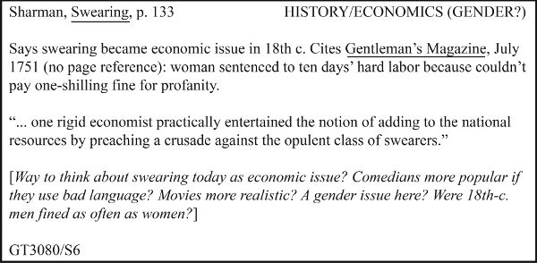

左上角是作者、简短标题和页码。右上角是关键词，方便研究人员将笔记分类和排序。卡片正文总结资料来源，记录直接引语（如适用），并包含研究人员的问题和解答。这样的卡片或许看起来有些过时，但它提供了一个高效的笔记模板：

At the top left is the author, short title, and page number(s). At the top right are keywords that let the researcher sort and re-sort notes into different categories and orders. The body of the card summarizes the source, records a direct quotation (where appropriate), and includes the researcher’s questions and responses. A card like this may seem old-fashioned, but it provides a template for efficient note-taking:

- ▪ 记录每个来源的完整书目信息，以便正确引用并轻松再次找到它。
- ▪ Record complete bibliographic information for each source so that you can cite it properly and find it again easily.
- ▪ 即使来自同一来源，也要对不同主题进行单独记录。
- ▪ Separate notes on different topics, even if they come from the same source.
- ▪ 务必确保笔记准确无误，因为之后需要用到。如果要引用多行文字，请复制或保存段落或整个文档。注意转录错误：手抄或打字引用时，即使你自认为很仔细，也很容易出错。（这种转录的风险也正是其优势所在——当你真正手写或打字引用，而不是简单地复制粘贴时，你必须认真思考。）
- ▪ Make sure your notes are accurate because you need to be able to rely on them later. If you want to quote more than a few lines, copy or save the passage or the whole document. Be alert for transcription errors: when hand-copying or typing out quotations, it is surprisingly easy to alter their wording, even when you think you are being careful. (This risk in transcription is tied to its benefit—when you actually write or type out a quotation, rather than just copying-and-pasting it, you have to think about it.)
- ▪ 不仅要记录来源的说法，还要记录你发现的任何数据或佐证。
- ▪ Record not only the source’s claim but any data or support you find interesting.
- ▪ 记录下你的赞同、反对、推测、疑问等等。你是否发现原文论证中存在任何复杂之处或矛盾之处？原文是否提出了任何问题？这将促使你超越简单的记录阅读内容。
- ▪ Note your agreements, disagreements, speculations, questions, and so on. Do you see any complications or contradictions in the source’s argument? Did the source raise any questions? That will encourage you to do more than simply record the content of what you read.
- ▪ *务必清晰*区分：(1) 引自原文的内容；(2) 转述或总结原文的内容；(3) 你自己的想法。如果用纸笔书写，请使用标题、括号或不同颜色的墨水来区分这些不同类型的笔记。如果使用电脑或在线记笔记，请使用不同的字体或颜色。你必须*明确*区分自己的文字和原文，因为两者很容易混淆。
- ▪ *Clearly* distinguish (1) what you quote from a source, (2) what you paraphrase or summarize from a source, and (3) your own thoughts. If you are writing on paper, use headings or brackets or different colors of ink to differentiate these different kinds of note. If you are using a computer or taking notes online, use different fonts or different colors of type. You must *unambiguously* distinguish your own words from those of your sources because it is so easy to confuse the two.

你或许会疑惑，既然可以直接用电子设备记录笔记，为什么还要费劲用纸笔呢？纸质笔记虽然存储、备份、索引和检索起来都很麻烦，但仍然有其用武之地。例如，笔记本或索引卡片价格低廉且便于携带，而且纸张有时能胜任科技无法企及的工作——有些档案馆仍然要求读者用纸笔做笔记。一些研究人员继续依赖纸质笔记的主要原因在于，它们有助于思考。由于不可能把所有内容都写下来，使用纸张会迫使你思考哪些内容最为重要。同样，如果你的笔记写在卡片或纸张上，你可以将它们分组、打乱顺序，或者摊放在桌子、台面甚至地板上。而且，*记录*笔记的过程本身不仅能帮助你记住笔记的内容，还能帮助你发现其中的联系，并发展出自己的想法。

Why, you might wonder, would anyone bother with paper notes when they could just type their notes into a device? As cumbersome as paper notes can be to store, back up, index, and access, they still have their uses. For example, a notebook or pack of index cards is cheap and portable, and paper can sometimes go where technology cannot—some archives still require patrons to take notes with paper and pencil. The main reason some researchers continue to rely on paper notes is that they help with thinking. Since you can’t write out everything, using paper forces you to think about what is most important. Likewise, if your notes are on cards or sheets of paper, you can group them, shuffle them, or lay them out on a desk, a table, or even the floor. And the very act of *writing out* your notes can help you not only remember what is in them but also see connections and develop your own ideas.

然而，如今很少有研究人员完全依赖纸质笔记。大多数人也会同时使用电子笔记，他们虽然会在纸上思考，但会利用电子笔记来确保引文、参考文献和注释的准确性。

Still, very few researchers today rely on paper notes alone. Most take notes electronically as well, thinking on paper but using electronic notes to ensure the accuracy of their quotations, references, and citations.

### 4.6.2 电子笔记

### 4.6.2 Taking Notes Electronically

当您使用电脑、平板电脑、手机或其他电子设备做笔记时，您有多种选择：

When you take notes using a computer, tablet, phone, or other electronic device, you have several options:

- 您可以使用 Word 或 Google Docs 等程序。为每个来源创建一个单独的文件（或至少单独一页），并确保为了明确区分自己的文字和来源文字，这类程序虽然易于使用，但也限制了你对笔记进行索引、整理、排序和搜索的能力。尤其对于篇幅较长或较为复杂的项目，你可能需要考虑其他方案。
- ▪ You can use a program like Word or Google Docs. Create a separate file (or at least a separate page) for each source, and be sure to unambiguously distinguish your own words from those of your source. Such programs are easy to use, but they also limit your ability to index, organize, sort, and search your notes. For long or complex projects especially, you may want to consider other options.
- 您可以使用专门的笔记应用程序来创建和整理笔记。这类应用程序可以帮助您索引、排序和访问笔记，但由于它们有时使用专有格式，因此可能会使您难以导出笔记或将其与其他程序一起使用。
- ▪ You can use a dedicated note-taking application to create and organize your notes. Such applications can help you to index, sort, and access your notes, but since they sometimes use proprietary formats, they can sometimes make it difficult for you to export your notes or use them with other programs.
- 您可以使用功能齐全的文献管理系统。除了帮助您做笔记外，这些程序通常还能直接从在线图书馆目录和数据库中提取信息，并在您写作时自动格式化和更新您的引文和参考文献。有些系统甚至会将您所有参考文献的完整电子版存储在参考文献管理系统中，帮助您构建和维护个人参考文献库。但与笔记应用程序一样，这些系统有时也使用专有格式——您需要学习如何使用它们。
- ▪ You can use a full-featured citation-management system. In addition to helping you make your notes, these programs can often pull information directly from online library catalogs and databases, and they can format and update your citations and bibliographies when you write. Some will even store full electronic copies of your sources within the reference-management system, helping you build and maintain your personal library of sources. But like note-taking applications, these systems sometimes use proprietary formats—and you have to learn to use them.

这三种类型的应用程序均提供网页版，这意味着应用程序和您的笔记并非存储在您自己的计算机上，而是存储在云端。这可以保护您的数据免遭意外丢失或损坏，并有助于您与其他研究人员共享信息和协作。

All three types of application are also available in web-based versions, meaning that the application and your notes reside not on your own computer but in the cloud. This protects your data from inadvertent loss or corruption and can help you share information and collaborate with other researchers.

但无论你使用什么技术，都必须考虑一些基本问题：

But whatever technology you use, you have to consider some basic questions:

- ▪ 你打算如何保持条理清晰？例如，如果你计划为每个资料来源创建一个单独的文档，那么你需要一个文件命名和存储系统。如果没有这样的系统，很容易在电脑或设备上“丢失”你的笔记。
- ▪ How will you stay organized? For example, if you plan to create a separate document for each source, you then need a system for naming and storing your files. Without such a system, it is very easy to “lose” your notes on your computer or device.
- ▪ 你将如何使用你的笔记？你可能会决定针对小型项目和大型项目、离散项目和持续性项目、个人项目和协作项目采用不同的笔记存储方式。
- ▪ How will you use your notes? You may decide to store your notes differently for small projects and large ones, for discrete projects and ongoing ones, for individual projects and collaborative ones.
- ▪ 你的学校或图书馆提供哪些应用程序？许多学校和图书馆都提供笔记软件或参考资料管理软件。这些系统面向教职员工、学生和用户，有时还会将这些工具与他们的目录集成在一起。如果您可以使用此类资源，请考虑使用它们。
- ▪ What applications are available through your school or library? Many schools and libraries offer note-taking or reference-management systems to faculty, students, and patrons, sometimes integrating these tools with their catalogs. If you have access to such resources, consider using them.
- ▪ 您打算如何备份笔记？无论您选择如何记录和整理笔记，请确保在出现意外情况时能够恢复它们：例如，咖啡洒在笔记本电脑上、手机丢失、文件与新版笔记应用不兼容、地下室的老鼠啃坏了索引卡片盒等等。我们建议您将笔记存储在云端，或者至少备份到云端。备份软件可以自动完成这些操作。
- ▪ How will you back up your notes? However you decide to take and organize your notes, make sure you can recover them if something goes wrong: you spill coffee on your laptop, you lose your phone, your files are incompatible with the new version of your note-taking app, mice in your basement chew through your box of index cards. Our suggestion is that you store your notes in, or at least back them up to, the cloud. Backup software can do this for you automatically.
- 最重要的是：哪种方法最适合你自己的写作、思考和工作方式？随着你写作和研究能力的提升，你会逐渐形成一套独特的个人工作方法。其他人可能会觉得这些方法繁琐、令人困惑，甚至难以理解。但这都没关系。记住，你的目标不是创建一套详尽的笔记，而是高效、有条理地进行研究和写作。如果一款软件不能帮助你做到这一点，那么对你来说，它就毫无用处。
- ▪ Most important: What approach best suits your own ways of writing, thinking, and working? As you grow as a writer and researcher, you will develop ways of working that are particular to you. Others may find them cumbersome or confusing or even incomprehensible. No matter. Remember that your goal is not to create an elaborate set of notes but to research and write capably and intelligently. If a piece of software doesn’t help you do that, it isn’t useful—to you.

### 4.6.3 决定引用、释义还是概括

### 4.6.3 Deciding Whether to Quote, Paraphrase, or Summarize

如果你能复印、扫描、下载或剪切粘贴资料来源，或者你知道写作时可以随时在线访问，那么你就可以把注意力从忠实还原原文转移到自己对资料的理解上。这是一个巨大的优势。总结资料来源，这也有助于你理解它，并记下你可能想要引用或转述的段落。同时，也要记录你对资料来源的回应。你发现自己在哪些方面赞同它的观点？哪些方面不赞同？你是否想说“*是的，但是……”？*

If you can photocopy, scan, download, or cut-and-paste your source, or you know that you can access it online when you write, you can focus less on preserving its exact words than on your own engagement with it. That’s a great advantage. Summarize the source, which will also help you understand it, and note passages you may want to quote or paraphrase when you write. Note also your own responses to the source. Where did you find yourself agreeing with it? Disagreeing? Wanting to say, *Yes, but . . . ?*

如果你无法保存完整的资料来源，也不确定以后是否还能访问，那么你将面临一个更艰难的选择：哪些部分需要完整记录（例如转录、剪切粘贴、截图或拍照），哪些部分需要概括或转述。在这种情况下，你必须考虑以后如何使用这些笔记。你的研究领域也会影响你的选择：人文学科的研究人员在写作时通常引用原文；社会科学家和自然科学家则通常采用转述和概括的方式（参见第12章）。

If you can’t preserve your entire source and don’t know whether you will be able to access it later, you have a tougher choice: what parts of the source to record exactly (by transcribing them, cutting-and-pasting, taking a screenshot, or snapping a photo) and what parts to summarize or paraphrase. In this situation, you have to consider how you plan to use your notes later. Your field will affect your choices: When they write, researchers in the humanities quote most often; social and natural scientists usually paraphrase and summarize (see chapter 12).

- ▪ 当您只需要了解一段文字、一个章节甚至整篇文章或一本书的要点时，可以使用摘要。摘要有助于了解与研究项目相关但并非直接相关的背景信息或观点。但请注意，摘要本身并不能作为有效的证据。
- ▪ Summarize when you need only the point of a passage, section, or even a whole article or book. Summary is useful for context or views that are related but not specifically relevant to your research project. A summary of a source never serves as good evidence.
- ▪ 当一段文字的具体用词不如其含义重要时，可以使用释义。释义并非仅仅改变一两个词，而是要用自己的语言替换原文的大部分词语和措辞。释义的证据效力永远不如直接引用。
- ▪ Paraphrase when the specific words of a passage are less important than its meaning. Paraphrasing doesn’t mean changing just a word or two. You must replace most of the words and phrasing of the original with your own. A paraphrase is never as good evidence as a direct quotation.
- ▪ 为实现以下目的，请记录准确的报价：
- ▪ Record exact quotations for these purposes:
- ——引用的文字是支持你论点的证据。例如，如果你声称不同群体对重新命名以奴隶主命名的建筑物的反应不同，你就应该引用不同新闻来源的原文。如果你只需要了解他们的总体观点，则可以进行意译。
- —The quoted words are evidence that backs up your reasons. If, for example, you claim that different groups respond differently to renaming buildings named for enslavers, you would quote exact words from different news sources. You would paraphrase them if you needed only their general sentiments.
- —这些话出自你打算依赖或质疑的权威人士之口。
- —The words are from an authority you plan to rely on or challenge.
- —这些话非常新颖独特，或者极具说服力，以至于这段引文可以作为你接下来讨论的框架。
- —The words are strikingly original or so compelling that the quotation can frame the rest of your discussion.
- —消息来源提出了你不同意的观点，为了公平起见，你想准确地陈述该观点。
- —The source makes a claim that you disagree with, and to be fair you want to state that claim exactly.

*千万不要*为了方便而缩写引语，以为之后就能准确地还原原文。你做不到。而且，如果你引用错误，就会损害你的信誉。

*Never* abbreviate a quotation thinking you can accurately reconstruct it later. You can’t. And if you misquote, you will undermine your credibility.

### 4.6.4 正确把握语境

### 4.6.4 Getting the Context Right

你不可能记录*所有内容*，但必须记录*足够的*信息，以确保准确捕捉到资料的含义。在使用资料时，不仅要记录他们说了什么，还要记录他们是如何运用这些信息的。

You can’t record *everything*, but you have to record *enough* to ensure that you accurately capture the source’s meaning. As you use material from your sources, record not just what they say but how they use the information.

1. 1.**引用、转述或概括时，务必注意语境。**你无法完全避免断章取义，因为你不可能引用原文的全部内容。因此，当你撰写转述、概括或复制引文时，务必将其置于最重要的语境中——即你对原文的理解。当你注意到重要的论点或结论，记录作者的推理过程：
   > 1. 注意：巴托利（第 123 页）：战争是由 Z 引起的。
   > 2. 注意：巴托利（第 123 页）：战争是由 X、Y 和 Z 引起的。
   > 3. 但是：巴托利：战争是由 X、Y 和 Z 引起的（第 123 页）。但最重要的原因是 Z（第 123 页），原因有二：首先，……（第 124-126 页）；其次，……（第 126 页）。
   > 4. 即使你只关心结论，如果你记录下作者得出结论的过程，你也能更准确地使用它。
   > 5. 2.**记录论点时，请注意它在原文中的作用。**它是主要论点？次要论点？限定条件或让步？通过记录这些区别，您可以避免此类错误：
   > 6. 琼斯原文 ： “研究人员认识到，肺癌的病因有很多，包括遗传倾向和接触石棉、氡、细颗粒物等环境因素。但研究过相关数据的人都一致认为，吸烟是肺癌的主要病因。”
   > 7. 关于 琼斯的误导性说明：吸烟只是导致肺癌的众多原因之一。例如，琼斯声称“肺癌的病因有很多，包括遗传倾向和接触石棉、氡和细颗粒物等环境因素。”
   > 8. 琼斯根本没有提出这一点。她*只是先*让步，引出她自己想要表达的观点。任何故意以这种方式歪曲事实的人都违反了基本的真相准则。但是，如果你只关注消息来源的措辞，而忽略了它们在论证中的作用，就可能无意中犯下这样的错误。
   > 9. 为避免此类错误，应区分论证的核心陈述与作者承认但淡化的限定或让步。除非你是在“反其道而行之”地解读作者的意图——例如，为了揭露其隐藏的倾向——否则不要将来源中的次要方面当作主要方面来报道，更不要将其当作来源的全部论点。
   > 10. 3.**记录声明的范围和置信度。**不要让声明看起来比实际情况更确定或影响范围更广。第二句话没有准确或公正地转述第一句话：
   > 11. 原文：一项关于风险感知的研究（Clark，2008）表明，高风险赌博与儿童脑震荡之间存在联系。
   > 12. 误导性说明 ：克拉克（2008 年）表示，儿童脑震荡会导致高风险赌博。
   > 13. 4.**不要将对其他作者观点的总结误认为是作者自身的总结。**有些作者并未明确指出他们何时在总结他人的论点，因此很容易将他们的观点理解为他们试图反驳的内容，而非他们实际的观点。
   > 14. 5.**注意不同信息来源的共识与分歧所在。信息来源达成共识的** *方式*和*原因与它们达成共识**本身*同样重要。同样，信息来源也可能因为对同一证据的解读不同或解决问题的方法不同而产生分歧。盲目相信任何一位研究者对某个问题的观点都是有风险的。不加批判地总结他人的研究成果并非真正的“研究”。即使你的信息来源广受信赖，也要谨慎。如果你至少参考两个信息来源，通常会发现它们并非完全一致，而这正是你开展独立研究的起点。*哪个论证更有说服力？哪个更尊重证据？*事实上，这本身就是一个研究问题：*我们应该相信谁？*
2. 1. **When you quote, paraphrase, or summarize, be careful about context.** You cannot entirely avoid quoting out of context, because you cannot quote all of an original. So when you draft a paraphrase or summary or copy a quotation, do so within the context that matters most—that of your own grasp of the original. When you note an important argument or conclusion, record the author’s line of reasoning:
   > 1. NOT: Bartolli (p. 123): The war was caused by Z.
   > 2. NOT: Bartolli (p. 123): The war was caused by X, Y, and Z.
   > 3. BUT: Bartolli: The war was caused by X, Y, and Z (p. 123). But the most important cause was Z (p. 123), for two reasons: first, . . . (pp. 124–26); second, . . . (p. 126).
   > 4. Even if you care only about a conclusion, you will use it more accurately if you record how an author reached it.
   > 5. 2. **When you record a claim, note its role in the original.** Is it a main point? A minor point? A qualification or concession? By noting these distinctions, you avoid this kind of mistake:
   > 6. ORIGINAL BY JONES: “Researchers recognize that lung cancer has a number of causes, including genetic predisposition and exposure to environmental factors such as asbestos, radon, and fine particulates. But no one who has studied the data doubts that lung cancer’s leading cause is smoking.”
   > 7. MISLEADING NOTE ABOUT JONES: Smoking is just one cause of lung cancer among many. Jones, for example, claims that “lung cancer has a number of causes, including genetic predisposition and exposure to environmental factors such as asbestos, radon, and fine particulates.”
   > 8. Jones did not make that point at all. She *conceded* a point to set up the point she wanted to make. Anyone who deliberately misreports in this way violates basic standards of truth. But you can make such a mistake inadvertently if you note only a source’s words and not their role in an argument.
   > 9. To avoid such mistakes, distinguish statements that are central to an argument from qualifications or concessions that the author acknowledges but downplays. Unless you are reading “against the grain” of the writer’s intention—to expose hidden tendencies, for example—do not report minor aspects of a source as though they were major or, worse, as if they were the source’s whole point.
   > 10. 3. **Record the scope and confidence of a claim.** Don’t make a claim seem more certain or far-reaching than it is. The second sentence doesn’t accurately or fairly report the first:
   > 11. ORIGINAL: One study on the perception of risk (Clark, 2008) suggests a link between high-stakes gambling and childhood concussions.
   > 12. MISLEADING NOTE: Clark (2008) says childhood concussions cause high-stakes gambling.
   > 13. 4. **Don’t mistake a summary of another writer’s views for those of an author summarizing them.** Some writers do not clearly indicate when they summarize another’s argument, so it is easy to quote them as saying what they set out to disprove rather than what they in fact believe.
   > 14. 5. **Note why sources agree and disagree.** *How* and *why* sources agree is as important as the fact *that* they do. In the same way, sources might disagree because they interpret the same evidence differently or take different approaches to the problem. It is risky to attach yourself to what any one researcher says about an issue. It is not “research” when you uncritically summarize another’s work. Even if your source is universally trusted, be careful. If you rely on at least two sources, you’ll usually find that they do not agree entirely, and that is where your own research can begin. *Which has the better argument? Which better respects the evidence?* In fact, you have a research problem right there: *Whom should we believe?*

## 4.7 注释你的资料来源

## 4.7 Annotating Your Sources

有一些技巧可以帮助你通过*注释系统地利用资料来源。*虽然机械地下载、剪切粘贴、复印或重新输入资料段落可以帮助你准确地引用或转述，但如果你不与资料来源进行互动，你只会积累一些毫无生气的数据，最终不得不费力地筛选它们。为了推进你的思考，请对关键句子和段落进行注释，例如高亮显示或添加标签，以便日后查找。标记你预期在论证中使用的观点或数据。总结你标记的内容或绘制草图。你可以对它做出回应，或者在页边空白处添加注释，帮助你理解你高亮的部分。你现在对某个资料的描述越多，以后就越能更好地理解它。

There are some techniques for engaging your sources systematically through *annotation*. While mechanically recording passages from sources by downloading, cutting-and-pasting, photocopying, or retyping can help you quote or paraphrase accurately, if you don’t talk back to your sources, you will simply accumulate inert data that you will have to sift through at some point. To advance your thinking, annotate key sentences and passages by highlighting or labeling them so that you can find them later. Mark ideas or data that you expect to use in your argument. Summarize what you have highlighted or sketch a response to it or add notes in the margin that help you interpret your highlighting. The more you write about a source now, the better you will understand it later.

### 4.7.1 边注

### 4.7.1 Marginal Annotations

除了在纸上或电脑上做笔记之外，您还可以直接对许多纸质或电子版资料进行注释。注释是一种通过评论、提问和与其他资料的交叉引用来标记资料的技术。在文本资料的页边空白处进行注释通常比简单地高亮显示更有效，因为它能更清晰地展现资料与您项目的相关性。

As an alternative to taking notes on paper or a computer, you can directly annotate many sources in print or digital form. Annotation is a technique of marking up a source through comments, questions, and cross-references to other sources. Annotating in the margins of textual sources is generally more productive than simply highlighting because it brings into relief the relevance of a source to your project.

在注释过程中，您可以记录本章讨论的积极阅读实践。您可以使用注释来识别资料的论点和关键词，或者通过质疑（或扩展）资料的理由、证据和论证来“论证”资料（参见第三部分）。随着项目的推进，您可以返回到已注释的资料，回顾您之前的思考。

In annotating, you document the active reading practices discussed in this chapter. You can use annotations to identify a source’s claims and keywords or “argue” with a source by questioning (or extending) its reasons, evidence, and warrants (see part III). As your project develops, you can return to an annotated source to see what you were thinking earlier.

当然，并非所有资源都同样适合注释。你不能在图书馆书籍或其他非自有文本的页边空白处做笔记。许多文本只能（或最方便地）以数字形式获取。不过幸运的是，有一些数字注释工具可以让你在数字环境中记录阅读内容。你可以使用这些工具注释各种资源，包括文本、图像等。录音、视频，并将您的回复与各种来源关联起来，创建一个可搜索的数据库，以便日后参考。

Of course, not every source is equally available for annotation. You can’t write in the margins of library books or other texts you do not own. Many texts are accessible only (or most conveniently) in digital form. Fortunately, however, there are digital annotation tools that let you document your reading in digital environments. You can use these tools to annotate a wide range of sources, including texts, images, recordings, and video, and to link your responses to various sources to create a searchable database for later reference.

广泛阅读的价值

The Value of Reading Widely

我们强调过，提出一个好问题对于聚焦研究至关重要。但不要以为阅读那些最终被证明无关的资料是浪费时间。事实上，当你阅读并记录的资料多于实际使用时，你就能积累起对有效思考至关重要的知识基础。有效思考是一种可以学习的技能，但只有拥有深厚而广泛的知识基础才能真正运用它。因此，阅读资料不仅是为了回答你今天提出的问题，更是为了帮助你更好地思考未来研究生涯中将会提出的每一个问题。从这个意义上讲，你阅读的每一份资料都具有价值。

We have emphasized how important it is to have a good question to focus your research. Don’t think, however, that you waste time reading sources that turn out to be irrelevant. In fact, when you read and record more than you use, you build up a base of knowledge crucial to the exercise of good thinking. Good thinking is a skill that you can learn, but you can exercise it only when you have a deep and wide base of knowledge to work with. So read sources not just to answer the question you ask today, but to help you think better about every question you’ll ask for the rest of your research career. To that end, everything you read is relevant.

### 4.7.2 注释书目

### 4.7.2 Annotated Bibliography

一种利用文献资料的方法是制作带注释的书目——一份列出所有可能文献的清单，每条文献都附有引文和简要概述。（关于引文的更多信息，请参见第12章。）根据创建注释的目的，注释可以分为多种类型。对于研究项目而言，带注释的书目能够提供一系列文献及其在论证中可能发挥的作用的概览。通常，编写带注释的书目是研究过程中的一个独立阶段，它使您（以及您的老师）有机会反思所收集的文献。每条注释都是一次评估文献可信度、总结其论点并解释其与项目相关性的机会。

One approach to engaging sources is an annotated bibliography—a list of possible sources featuring a citation and brief summary for each source. (For more on citations, see chapter 12.) There are multiple types of annotations based on the motive for creating them. For a research project, an annotated bibliography offers a bird’s-eye view of a range of sources and the roles they might play in your argument. Often the assembling of an annotated bibliography is a distinct stage in a research process, one that allows you (and your teacher) to reflect on the sources you have collected. Each annotation is an opportunity to evaluate the credibility of a source, summarize its argument, and explain its relevance to your project.

编制带注释的书目可以帮助你评估你的研究是否彻底，以及你对收集到的资料的运用是否深入。

Compiling an annotated bibliography can help you gauge how thoroughly you have conducted your research and how deeply you have engaged the sources you have collected.

### 4.7.3 用于对笔记进行分类和整理的关键词

### 4.7.3 Keywords That Categorize Your Notes for Sorting

最后，一项概念性挑战：在做笔记时，请将每条笔记归类到两个或多个关键词下（参见第 85 页笔记卡的右上角）。不要机械地使用原文中的词语；要根据笔记对你问题的启示，以及超越其具体内容的更宏观的概念来对其进行分类。对相关的笔记使用相同的标签或关键词；不要为每条新笔记都创建一个新的标签或关键词。

Finally, a conceptually challenging task: as you take notes, categorize each one under two or more keywords (see the upper-right corner of the note card on p. 85). Don’t mechanically use words from the source; categorize the note by what it implies for your question, by a general idea larger than its specific content. Use the same tags or keywords for related notes; don’t create a new one for every new note.

这一步至关重要，因为它能迫使你找出笔记的核心思想。如果你用电子设备做笔记，关键词可以让你通过一次查找命令就将相关的笔记归类。如果你使用多个关键词，就可以用不同的方式重新组合笔记，从而发现新的关联（这在你感觉思路混乱时尤为重要）。

This step is crucial because it forces you to find the central ideas in a note. If you take notes electronically, the keywords let you instantly group related notes with a single Find command. If you use more than one keyword, you can recombine your notes in different ways to discover new relationships (especially important when you feel you are spinning your wheels).

▶ 小贴士：如何应对不确定时刻

▶ Quick Tip: Managing Moments of Uncertainty

随着项目深入，你可能会遇到这样的时刻：所有事情似乎都混成一团，让人束手无策。这种情况通常发生在你积累笔记的速度超过了整理的速度时。这样的时刻固然令人焦虑，但也可能预示着你即将获得新的洞见或发现。

As you get deeper into your project, you may experience a moment when everything seems to run together into a hopeless muddle. That usually happens when you accumulate notes faster than you can sort them. Such moments can be stressful, but they can also be a sign that you are on the verge of a new insight or discovery.

你可以抓住一切机会整理和总结你收集到的信息，边*做边写*，并不断回到核心问题上，从而最大限度地减少焦虑：*我提出的问题是什么？我提出的难题是什么？*反复练习这个公式：*我正在研究 X，以了解更多关于 Y 的信息，这样我的读者就能更好地理解 Z。*定期记录这些问题不仅能帮助你保持专注，还能帮助你思考。

You can minimize anxiety by taking every opportunity to organize and summarize what you have gathered by *writing as you go* and by returning to the central questions: *What question am I asking? What problem am I posing?* Keep rehearsing that formula, *I am working on X to learn more about Y, so that my audience can better understand Z.* Writing regularly about these questions does more than help you stay focused; it also helps you think.

你还可以向朋友、同学、老师——任何愿意倾听你想法但又能提出批评意见的人——寻求帮助。解释你所学到的知识如何与你的问题相关，以及如何帮助你解决问题。问问他们：“*这样说得通吗？我是否遗漏了什么重要的信息？你们还想知道什么？”*他们的反馈会让你受益匪浅，但更重要的是，向非专业人士解释你的想法本身就会让你受益匪浅。

You can also turn to friends, classmates, teachers—anyone who will serve as a sympathetic but critical audience. Explain how what you have learned bears on your question and helps you solve your problem. Ask them, *Does this make sense? Am I missing anything important? What else would you like to know?* You will profit from their reactions, but even more from the mere act of explaining your ideas to non-specialists.

# 第三部分

# Part III

# 提出你的论点

# Making Your Argument

# 序幕

# Prologue

# 构建研究论点

# Assembling a Research Argument

你不能等到收集齐所有数据、找到所有相关资料后才开始规划论证。首先，你永远不可能全部收集到。其次，你最终只会机械地、漫无目的地研究，积累越来越多的资料却不知其用，或者像无头苍蝇一样四处乱窜。当然，你需要做一些研究来掌握项目的脉络。但一旦你对问题及其可能的解决方案有了清晰的认识，就应该开始规划论证。随着研究的深入，你的计划也会随之改变——如果计划一成不变，说明你可能没有进行充分的思考——但尽早制定计划并根据研究进展不断调整，能帮助你更好地理解材料，更有针对性地进行研究。只有当你尝试构建一个*能够回答听众预期问题的论证*时，你才能发现自己还有哪些研究工作尚未完成。

You can’t wait to plan your argument until after you’ve gathered every last bit of data and found every last relevant source. In the first place, you’ll never get them all. In the second, you’ll end up researching mechanically or aimlessly, accumulating more and more stuff with no sense of what you’ll do with it or following trails of bread crumbs who knows where. Of course, you have to do some research to get a handle on your project. But as soon as you have a sense of your problem and its likely solution, you should begin planning your argument. Your plan will change as your research progresses—if it doesn’t, you probably aren’t doing your best thinking—but making a plan early and modifying it as you go will help you grasp your material better and research more purposefully. Only when you try to make a *research argument* that answers your audience’s predictable questions can you see what research you have yet to do.

学术争论与我们日常生活中听到的激烈争吵截然不同。那些争论通常涉及纠纷：孩子们为了一个玩具争吵，室友们争论灯开到多晚，司机们争论谁有优先通行权。这类争论可能礼貌，也可能粗鲁，但大多数都包含冲突，有输有赢。诚然，研究人员有时也会就彼此的推理和证据争论不休，偶尔还会指责对方粗心、无能，甚至欺诈。但正是这类争论，并非他们最初选择成为研究人员的原因。

A research argument is not like the heated exchanges we hear every day. Those arguments usually involve a dispute: children argue over a toy, roommates over how late to keep the lights on, drivers over who had the right-of-way. Such arguments can be polite or nasty, but most involve conflict, with winners and losers. To be sure, researchers sometimes wrangle over each other’s reasoning and evidence and occasionally erupt into charges of carelessness, incompetence, and even fraud. But that kind of argument is not what made them researchers in the first place.

接下来的五章，我们将探讨一种论证方式，它不像是一场充满争执、分出胜负的辩论，而更像是与友善且有时略带怀疑的同事们进行的一场生动对话。在这种对话中，你和你的假想听众*共同寻求*问题的答案：其目标并非一方强迫另一方同意，而是让每个人都能增进理解和知识。从这个意义上讲，最佳答案往往不是那些终结对话的答案，而是那些能够引发新问题、新探究和新论点的答案。

In the next five chapters, we examine a kind of argument that is less like a prickly dispute with winners and losers and more like a lively conversation with amiable and sometimes skeptical colleagues. It is a conversation in which you and your imagined audience *cooperatively* seek answers to shared questions: the goal is not for one side to coerce the other into agreement but for everyone to grow in understanding and knowledge. In this sense, the best answers are often not those that end the conversation but those that generate new questions, inquiry, and arguments.

然而，在那种对话中，你们做的远不止是礼貌地交换意见。我们都有权发表自己的意见，也没有任何法律要求我们解释或捍卫自己的意见。但在学术论证中，我们需要向读者展示我们论点的重要性，然后用充分的理由和证据来支持我们的论点，并回答“*我为什么要相信这一点？”这个相当合理的问题。*

In that conversation, though, you do more than politely trade opinions. We are all entitled to our opinions, and no law requires us to explain or defend them. But in a research argument, we are expected to show an audience why our claims are important and then to support our claims with good reasons and evidence, responding to the quite reasonable question *Why should I believe that?*

事实上，虽然我们更容易注意到激烈的争论，但我们每天都在进行这种合作式的讨论，每次我们交换合理的理由来决定做什么时——比如和朋友讨论买哪款手机、读哪本书，甚至是点披萨还是泰国菜。就像这些友好的讨论一样，研究论证并不强迫任何人接受某种观点。相反，你要从你的受众出发，从他们预期的疑问开始，询问他们为什么要接受你的观点。他们提出这些问题并非为了破坏你的论证，而是为了检验它，帮助你们双方找到并理解一个值得分享的真理。当然，当你*撰写*论证时，没有人会当面问你这些问题。所以你必须站在受众的角度去设想这些问题。正是这些设想的问题和你的答案，使你的论证成为持续对话的一部分。在第五章中，我们将概述构成研究论证的要素。在第六章到第九章中，我们将详细解释每个要素。在第四部分，我们将向你展示如何将论证转化为书面或演示文稿。

In fact, although we more easily notice the heated disputes, we have these collaborative arguments every day, each time we trade good reasons for deciding what to do—when discussing with a friend what cell phone to buy, what books to read, even whether to order pizza or Thai food. Like those friendly discussions, a research argument doesn’t force a claim on anyone. Instead, you start where your audience does, with their predictable questions about why they should accept your claim, questions they ask not to sabotage your argument but to test it, to help both of you find and understand a truth worth sharing. Of course, when you *write* an argument, no one is there to ask you those questions in person. So you must imagine them on your audience’s behalf. It’s those imagined questions and your answers that make your argument part of an ongoing conversation. In chapter 5, we survey the elements that constitute a research argument. In chapters 6–9, we explain each element in detail. In part IV, we’ll show you how to put that argument into writing or a presentation.

了解你

Getting to Know You

你或许无数次被告知要考虑受众，但没有什么比想象一个陌生人会提出的问题更难的了。经验丰富的研究人员的优势在于，他们认识研究群体中的许多成员，因此也认识他们的受众。他们会与这些成员讨论研究项目，在撰写论文之前尝试各种想法。如果你是一名初级研究人员或学生，你可能还没有这种与受众的密切联系。但你可以做一些功课，了解他们的写作、论证和思考方式：

You’ve been told endlessly to think about your audience, but nothing is harder than imagining questions from someone you don’t know. Experienced researchers have the advantage of knowing many members of their research communities, and thus their audiences, personally. They talk with them about research projects, trying out ideas before writing them up. If you are a beginning researcher or a student, you may not yet know your audience in this personal way. But you can do some homework to understand how they write, argue, and think:

- ▪ 阅读发表与你的研究类似的期刊。注意文章提出的问题类型以及它们引发的问题类型。
- ▪ Read journals that publish research like yours. Notice the kinds of questions the articles ask and the kinds of problems they raise.
- ▪ 与经验更丰富的研究人员或老师一起演练你的论点。在你有了计划但在起草之前，讨论你的想法，问问他们是否有任何让你感到怀疑或困惑的地方。
- ▪ Rehearse your argument with a more experienced researcher or a teacher. After you have a plan but before you draft, talk over your ideas, asking whether any seem doubtful or confusing.
- 写作时，请几位你信任的人阅读你的草稿，并指出他们提出的问题或建议。尽量找到与你的目标读者群体相似的人。
- ▪ When writing, ask a few people you trust to read your drafts and indicate where they have questions or see alternatives. Find people as much like your intended audience as possible.

你甚至可以尝试去结识一些真正的目标受众。例如，一群物理学家曾经希望生物学家关注他们的研究，但当他们投稿的第一篇生物学期刊论文被拒后，他们感到非常沮丧。于是，他们开始参加生物学会议，阅读生物学期刊，甚至经常出入生物系的教师休息室。在了解了生物学家的思维方式后，他们修改了论文，并发表了对该领域产生深远影响的论文。如果你是一名学生，你可能无法参加会议或在教师休息室闲逛，但你仍然可以结识校园里从事你所在领域研究的教师和学生。你对他们了解得越多，就越能更好地想象他们可能会问你的问题。

You can even try to get to know some actual members of your audience. For example, a group of physicists once wanted biologists to notice their research but were unhappy when the first manuscript they sent to a biology journal was rejected. So they started attending biology conferences, reading biology journals, even hanging around the biology department’s faculty lounge. After they figured out how biologists think, they rewrote their arguments and published papers that influenced the field. If you are a student, you may not be able to travel to conferences or hang out in a faculty lounge, but you can still get to know faculty and students on your campus working in your field. The better you know them, the better you will be able to imagine questions they might ask you.

# 5. 如何提出有力的论点

# 5 Making Good Arguments

# 概述

# An Overview

本章我们将解释什么是研究论证，以及构成研究论证的五个问题的答案。

In this chapter, we explain what a research argument is and the five questions whose answers constitute one.

在第一部分中，我们解释了真正的研究不仅仅是收集关于某个主题的信息；它意味着要针对你和你的受众所关心的问题提出解决方案。同样，分享你的研究成果也不仅仅是向受众“倾倒数据”，说“*以下是关于我的主题的一些事实*” ；它意味着要解释你的问题，并在研究论证中论证你的解决方案。

In part I, we explained that authentic research involves more than just amassing information on a topic; it means developing solutions to problems you and your audience care about. Likewise, sharing the results of your research involves more than just giving your audience a “data dump” that says, *Here are some facts about my topic*; it means explaining your problem and justifying your solution in a *research argument*.

## 5.1 论证即对话

## 5.1 Argument as Conversation

在研究论证中，你需要提出*论点*，用基于*证据的理由*支持它*，**承认*并回应*其他*观点，有时还需要解释你的*推理*原则。这些并不神秘。想想你每天都会进行的对话：

In a research argument, you make a *claim*, support it with *reasons* based on *evidence*, *acknowledge* and *respond* to other views, and sometimes explain your *principles* of reasoning. There’s nothing arcane about these things. Consider the kind of conversation you have every day:

艾比：我听说你上学期过得很艰难。你觉得这学期会怎么样？（*艾比以提问的形式提出了一个问题。*）

Abby: I hear you had a hard time last semester. How do you think this one will go? [*Abby poses a problem in the form of a question.*]

布雷特：希望好些了。[*布雷特回答了问题。* ]

Brett: Better, I hope. [*Brett answers the question.*]

艾比：怎么说？（*艾比要求布雷特给出相信他回答的理由。*）

Abby: How so? [*Abby asks for a reason to believe Brett’s answer.*]

布雷特：我正在修读专业课。[*布雷特解释了原因。* ]

Brett: I’m taking courses in my major. [*Brett offers a reason.*]

艾比：比如什么？（*艾比要求布雷特拿出证据来支持他的说法。*）

Abby: Like what? [*Abby asks for evidence to back up Brett’s reason.*]

布雷特：艺术史，设计导论。[*布雷特提供了证据来支持他的观点。* ]

Brett: History of Art, Intro to Design. [*Brett offers evidence to back up his reason.*]

艾比：为什么修读专业课会有帮助？（*艾比认为布雷特的理由与他声称自己会做得更好毫无关联。*）

Abby: Why will taking courses in your major make a difference? [*Abby doesn’t see the relevance of Brett’s reason to his claim that he will do better.*]

布雷特：当我选修自己感兴趣的课程时，我会更加努力。[*布雷特提出了一个普遍原则，将他的理由与他会做得更好的说法联系起来。* ]

Brett: When I take courses I’m interested in, I work harder. [*Brett offers a general principle that relates his reason to his claim that he will do better.*]

艾比：那你还得修那门数学课呢？（*艾比不同意布雷特的理由。*）

Abby: What about that math course you have to take? [*Abby objects to Brett’s reason.*]

布雷特：我知道上次我选这门课的时候不得不放弃，但我现在有个很好的家教。[*布雷特承认艾比的反对意见并作出了回应。* ]

Brett: I know I had to drop it last time I took it, but now I have a good tutor. [*Brett acknowledges Abby’s objection and responds to it.*]

如果你能设身处地地想象自己置身于那场对话中，你就会发现构建研究论证并不奇怪。这是因为任何论证的五个要素，实际上都是对艾比向布雷特提出的那些问题的回答——而这些问题，你也必须代表你的听众向自己提出：

If you can imagine yourself in that conversation, you’ll find nothing strange about assembling a research argument. That’s because the five elements of any argument are just answers to the kinds of questions that Abby asks Brett—and that you must ask yourself on your audience’s behalf:

1. 1.**论点：** *你想让我相信什么？你的观点是什么？*
2. 1. **Claim:** *What do you want me to believe? What’s your point?*
3. 2.**理由：** *你为什么这么说？我为什么要同意？*
4. 2. **Reasons:** *Why do you say that? Why should I agree?*
5. 3.**证据：** *你怎么知道？你能证明吗？*
6. 3. **Evidence:** *How do you know? Can you back it up?*
7. 4.**论证：** *这是如何得出的结论？你能解释一下你的理由吗？*
8. 4. **Warrant:** *How does that follow? Can you explain your reasoning?*
9. 5.**确认与回应：** *但是……呢？*
10. 5. **Acknowledgment and Response:** *But what about . . . ?*

把你的研究看作是找出这些问题答案的过程。

Think of your research as the process of figuring out answers to these questions.

## 5.2 构建论证的核心

## 5.2 Assembling the Core of Your Argument

每个研究论证的核心都包含三个要素：你的论点、你接受该论点的理由，以及支撑这些理由的证据。在此基础上，你可能需要添加一到两个要素：一是需要你证明自身推理合理性的论证（参见第八章），二是承认并回应提出的问题、反对意见和不同观点（参见第九章）。你可以将这些要素想象成对听众可能提出的常见问题的解答。

At the core of every research argument are three elements: your claim, your reasons for accepting it, and the evidence on which those reasons are based. To that core you’ll add one and perhaps two more elements: warrants where you need to justify your reasoning (see chapter 8) and acknowledgments of and responses to questions, objections, and alternative points of view (see chapter 9). Imagine these elements as answers to the predictable questions an audience will ask.

### 5.2.1 用理由支持主张

### 5.2.1 Support Claims with Reasons

第一种论据，即理由，是指引导听众接受你的观点的陈述。我们通常会在理由前加上“*因为”* ：

The first kind of support, a reason, is a statement that leads an audience to accept your claim. We often join a reason to a claim with *because*:

> Elementary schools should make teaching multiple languages a priority<sub>claim</sub> because we acquire languages best and most easily when we are young.<sub>reason</sub>

通常你需要不止一个理由来支持你的论点，而在复杂的论证中，你的理由通常还需要更多理由的支持：

You often need more than one reason to support a claim, and in a complex argument, your reasons will usually require support from still more reasons:

> 小学应将多语言教学作为优先<sub>事项（论点</sub>1） ，因为我们在年幼时最容易、最好地习得语言。 <sub>（理由</sub>1支持论点1/论点2）事实上，成年后才开始学习新语言的人，很少能达到从小学习语言的人的流利程度。 <sub>（理由</sub>2支持理由1和论点2/论点3）小学阶段教授多语言也有助于儿童的道德发展（理由3<sub>支持论点1/论点4），因为它能</sub>培养他们对自身文化和社会之外的其他文化和社会的认识。（理由4<sub>支持理由3和论点4/论点5）</sub>

> Elementary schools should make teaching multiple languages a priority<sub>claim 1</sub> because we acquire languages best and most easily when we are young.<sub>reason 1 supporting claim 1/claim 2</sub> In fact, those who begin new languages as adults rarely attain the level of fluency of those who learn them as children.<sub>reason 2 supporting reason 1 and claim 2/claim 3</sub> Teaching multiple languages at the elementary school level also contributes to children’s ethical development<sub>reason 3 supporting claim 1/claim 4</sub> because it fosters an awareness of cultures and societies beyond their own.<sub>reason 4 supporting reason 3 and claim 4/claim 5</sub>

### 5.2.2 基于证据的理由

### 5.2.2 Base Reasons on Evidence

第二种支撑是支撑你论点的证据。我们说过，论点往往需要其他论点的支持，但这种支持链不会无限延伸。最终，你必须拿出一些具体的数据或信息。这就是你的证据。论点和*证据这两个词*有时似乎可以互换使用：

The second kind of support is the evidence on which you base your reasons. We’ve said that reasons often require support from additional reasons, but these chains don’t go on forever. Eventually you have to show some concrete data or information. That’s your evidence. The terms *reasons* and *evidence* sometimes seem interchangeable:

> 你提出这一说法的依据是什么？

> 你的说法基于什么证据？

> On what reasons do you base your claim?

> On what evidence do you base your claim?

但它们的意思不同。请比较以下两个句子：

But they mean different things. Compare these two sentences:

> 你的理由基于什么证据？

> 你的证据依据是什么？

> On what evidence do you base your reasons?

> On what reasons do you base your evidence?

第二句话很奇怪：我们不以理由为依据来论证，而是以证据为依据来论证。我们*构思*理由：这些理由是用来支持我们论点的陈述。我们必须在现实世界中*寻找证据，然后让所有人都能看到。证据*证据是指我们用来支撑论点的各种信息或数据——统计数据、例子、引文、图片、模型等等。论点需要证据的支持；而证据本身则无需其他支持，只需严谨的论证或可靠来源的引用即可。

That second sentence is odd: we don’t base evidence on reasons; we base reasons on evidence. We *think up* reasons: they are statements that support our claims. We have to *search* for evidence “out there” in the world and then make it available for everyone to see. Evidence is the information or data—statistics, examples, quotations, images, models, and so on—that we use to back up our reasons. Reasons need the support of evidence; evidence should need no support beyond careful demonstration or a reference to a reliable source.

澄清一些术语

Clarifying Some Terms

到目前为止，我们用了两个术语来指代你在论证中提出的观点。在提问的语境中，我们称之为“*答案”。*在解决问题的语境中，我们称之为“*解决方案”* 。现在，在论证的语境中，我们将称之为“*主张”*。

So far, we’ve used two terms to name the statement that expresses the idea you are advancing in your argument. In the context of questions, we called it your *answer*. In the context of problems, we called it your *solution*. Now in the context of an argument, we’ll call it your *claim*.

- 论点是*指*需要论证支持的断言（可以是一句话或多句话）：*大熊猫是熊的一种*；*医疗保险支出将继续增长*；*托妮·莫里森最重要的小说是*《宠儿》。你的*主要论点*是你整个研究论证所支持的断言。有些人称这个断言为你的*主要观点*或*论文主题*。
- ▪ A *claim* is an assertion (which can be a single sentence or more) that demands support: *The giant panda is a species of bear*; *Medicare spending will continue to rise*; *Toni Morrison’s most important novel is* Beloved. Your *main claim* is the assertion that your whole research argument supports. Some call this assertion your *main point* or your *thesis*.
- 理由是支持某个主张的断言：*[因为]基因检测表明其他熊是它们最近的亲属；[**因为*]美国人口正在老龄化；[因为*]在*《宠儿》*，**莫里森的主要主题得到了最充分的发展。*
- ▪ A *reason* is an assertion that supports a claim: *[Because] genetic testing shows that other bears are their closest relatives*; *[Because] the US population is aging*; *[Because] in* Beloved, *Morrison’s major themes find their fullest development.*
- 证据 *是*用来支持某个理由的信息。与主张或理由不同，证据并不总是以断言的形式出现：例如，显示大熊猫与其他熊类在基因和解剖结构上相似性的数据；记录过去二十年美国居民年龄中位数的图表或数据表；以及*《宠儿》*用来阐释莫里森主要主题的引文，这些都是证据的形式。
- ▪ *Evidence* is information deployed to support a reason. Unlike a claim or a reason, evidence is not always framed as an assertion: figures showing the genetic and anatomical similarities between giant pandas and other bears; a chart or data table documenting the median age of US residents over the past twenty years; quotations from *Beloved* illustrating Morrison’s major themes would be forms of evidence.

这些区别可能令人困惑，因为主张和理由都是断言，而理由和证据也都是支撑。但如果你继续往下看，就会明白它们为何重要。

These distinctions might be confusing, because claims and reasons are both assertions, and reasons and evidence are both kinds of support. But if you stick with us, you’ll see why they matter.

在日常对话中，我们通常只用理由来支持自己的观点：

In casual conversation, we usually support a claim with just a reason:

> 我们应该走了。<sub>理由：</sub><sub>看起来</sub>要下雨了。

> We should leave.<sub>claim</sub> It looks like rain.<sub>reason</sub>

很少有人会问：*“你有什么证据证明看起来像下雨了？”*但在研究论证中，你也必须提供证据，因为谨慎的听众不会轻易接受表面原因：

Few ask, *What’s your evidence that it looks like rain?* But in a research argument you also have to give evidence because a careful audience won’t accept reasons at face value:

> 小学应该将多语言教学作为优先<sub>事项（论点</sub>1） ，因为我们在年幼时学习语言的效果最好、最容易。 <sub>（理由</sub>1支持论点1/论点2）事实上，成年后才开始学习新语言的人，很少能达到从小学习新语言的人的流利程度。 <sub>（理由</sub>2支持理由1/论点3 ）琼斯（2013）在一项针对一百多名语言学习者的研究中发现，新语言熟练程度与……呈负相关（见表1）。（<sub>证据支持理由2）</sub>

> Elementary schools should make teaching multiple languages a priority<sub>claim 1</sub> because we acquire languages best and most easily when we are young.<sub>reason 1 supporting claim 1/claim 2</sub> In fact, those who begin new languages as adults rarely attain the level of fluency of those who learn them as children.<sub>reason 2 supporting reason 1/claim 3</sub> In a study of over one hundred language learners, Jones (2013) identified an inverse correlation between new-language proficiency and . . . (see table 1).<sub>evidence supporting reason 2</sub>

但在大多数情况下，仅凭这一核心内容是不够的：你还需要通过（有时）提供*论据来充实你的研究论点*，以表明某个理由*与某个*主张的相关性，并通过*承认*和回应其他观点来充实你的研究论点。

But in most cases, this core alone isn’t enough: you also have to flesh out your research argument by (sometimes) offering *warrants* that show how a reason is *relevant* to a claim and by *acknowledging and responding* to other points of view.

## 5.3 解释你的论证理由

## 5.3 Explaining Your Reasoning with Warrants

即使你的听众认同某个理由是正确的，如果他们看不出这个理由*与*你的论点有何关联，他们仍然可能会感到困惑甚至反对。请思考以下论点：

Even when your audience agrees that a reason is true, they may still be puzzled or even object if they cannot see its *relevance* to your claim. Consider this argument:

> 由于近期国债收益率曲线出现倒挂，经济衰退<sub>似乎很有可能</sub><sub>发生</sub>。

> Since the yield curve in Treasury bonds recently inverted,<sub>reason</sub> a recession seems likely.<sub>claim</sub>

对金融和投资不熟悉的人可能会疑惑：*为什么收益率曲线倒挂会导致经济衰退？我看不出这两者之间有什么联系。*要回答这个问题，你必须解释你的推理过程，并提出一个能将你的*具体理由*与你的*具体论断联系起来的**普遍*原则：

Someone unfamiliar with finance and investing might wonder, *Why does that inverted yield curve make a recession likely? I don’t see the connection.* To answer, you must explain your reasoning by offering a *general* principle that connects your *particular* reason to your *particular* claim:

> 嗯，至少从20世纪中叶开始，国债收益率曲线倒挂就一直能可靠地预测即将到来的经济衰退<sub>。</sub>

> Well, since at least the mid-twentieth century, an inversion in the yield curve for Treasury bonds has reliably predicted coming recessions.<sub>warrant</sub>

这项论证表达了从经验中得出的原则，即收益率曲线倒挂预示着未来经济形势严峻。如同所有论证一样，它确立了（如果为真）我们可以从某种普遍情况（收益率曲线倒挂）推断出某种普遍后果（经济衰退的可能性）。如果一项主张是该普遍后果的恰当例证，而其理由又是该普遍情况的恰当例证，那么该论证便成立。

This warrant expresses the principle, learned from experience, that inverted yield curves are a sign of rough economic times ahead. Like all warrants, it establishes (if true) that we can infer some general consequence (likelihood of a recession) from some general circumstance (an inverted yield curve). If a claim is a good instance of that general consequence, and its reason is a good instance of that general circumstance, then the argument follows.

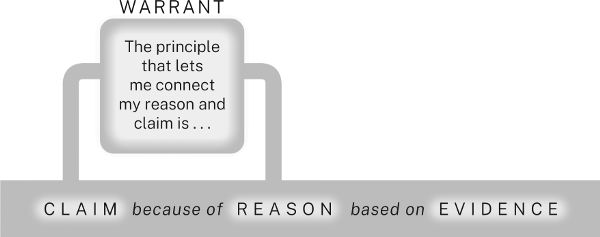

正如我们将在第八章中看到的，何时需要提供论证并非易事。经验丰富的研究人员通常只在两种情况下提出论证：一是当他们认为本领域的读者可能会质疑某个理由与论点之间的关联性时；二是当他们向普通读者解释本领域的推理方式时。

As we’ll see in chapter 8, it’s not easy to decide when you even need a warrant. Experienced researchers usually state them on only two occasions: when they think an audience in their field might ask how a reason is relevant to a claim or when they are explaining their fields’ ways of reasoning to a general audience.

## 5.4 识别并回应预期的问题和异议

## 5.4 Acknowledging and Responding to Anticipated Questions and Objections

细心的听众会质疑你论点的*每一个*细节，所以你必须尽可能地预判他们的问题，然后回应其中最重要的几个。例如，当听众思考“学校应该优先教授语言”这一观点时，他们可能会担心这样做是否会影响其他学科的教学。如果你认为他们可能会问这个问题，那么明智的做法是承认并回应它。

Careful audiences will question *every* part of your argument, so you must anticipate as many of their questions as you can and then acknowledge and respond to the most important ones. For example, when an audience considers the claim that schools should make language instruction a priority, they may wonder if doing that might detract from the teaching of other subjects. If you think they might ask that question, you would be wise to acknowledge and respond to it:

> 小学应该将多语言教学作为优先事项<sub>（论点</sub>1） ，因为我们在年幼时学习语言的效果最好、最容易。 <sub>（理由</sub>1支持论点1/论点2） ……当然，如果学校增加对语言教学的重视程度，其他学科的教学质量可能会下降。 <sub>（承认）</sub>但几乎没有证据支持这种担忧，而且有大量证据可以消除这种担忧。……<sub>回应</sub>

> Elementary schools should make teaching multiple languages a priority<sub>claim 1</sub> because we acquire languages best and most easily when we are young.<sub>reason 1 supporting claim 1/claim 2</sub> . . . Of course, if schools increase the attention they give to languages, quality of instruction in other subjects might decline.<sub>acknowledgment</sub> But little evidence exists to support that fear and much dispels it. . . .<sub>response</sub>

任何研究论证都离不开致谢和回应，因此我们将它们添加到图表中，以显示它们与论证所有其他部分的关系：

No research argument is complete without acknowledgments and responses, so we add them to our diagram to show how they relate to all the other parts of an argument:

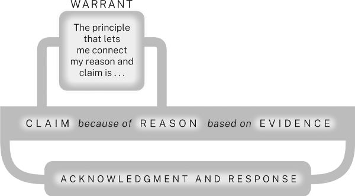

## 5.5 规划你的研究论点

## 5.5 Planning Your Research Argument

研究论证与日常论证一样，都包含五个要素：主张、理由、证据、论证依据以及对其他观点的承认和回应。只是研究论证更为复杂。除了主要主张之外，研究论证可能包含若干次要主张。而每个次要主张都可能得到其他理由和证据的支持，并可能由一个或多个论证依据来证明其合理性。研究论证几乎肯定会承认并回应预期的问题、替代方案和反对意见，而对每一种回应都需要单独的论证。

Research arguments are composed of the same five elements as everyday arguments: claims, reasons, evidence, warrants, and acknowledgments of and responses to other views. They are just more complex. In addition to its main claim, a research argument may include a number of subordinate claims. And each of these claims is likely to be supported by additional reasons and evidence and perhaps justified by one or more warrants. It will almost certainly acknowledge and respond to anticipated questions, alternatives, and objections, with each of these responses demanding its own argument.

最后，大多数研究论证都包含背景、定义、对受众可能不理解的问题的解释等等。例如，如果你要向一群不熟悉经济理论的听众阐述通货膨胀和货币供应之间的关系，你就必须解释经济学家是如何理解这些概念的。严谨的论证结构复杂，但只要将其分解成更简单的部分，就能驾驭自如。

Finally, most research arguments include background, definitions, explanations of issues that an audience might not understand, and so on. If, for example, you were making an argument about the relationship between inflation and money supply to an audience unfamiliar with economic theory, you would have to explain how economists understand those concepts. Serious arguments are complex constructions, but you can manage them if you break them down into simpler ones.

为了规划你的论证，你可以制作传统的提纲，也可以用其他方式将论证可视化。我们推荐使用类似图表的提纲或视觉组织工具，称为*故事板。*故事板就像一个被拆分成多个部分并分布在多页上的提纲，留有大量空间供你随时添加数据和想法。故事板比提纲更灵活。你可以使用应用程序或在线工具创建故事板，也可以像我们一样，使用索引卡片、便签或纸张。要开始制作故事板，请在每张卡片或页面的顶部写下你的主要论点以及每个理由（和子理由）。然后在每个理由（或子理由）下方，列出支持它的证据。如果你还没有证据，请记*下*你需要哪些类型的证据。如果你预计需要解释你的理由如何支持其论点，请添加一页来阐述其论证依据。你还可以添加页面来承认其他观点并做出回应。

To plan your argument, you can make a traditional outline or visualize your argument in other ways. We recommend using a chart-like outline or visual organizer known as a *storyboard*. A storyboard is like an outline broken into pieces and spread over several pages, with lots of space for adding data and ideas as you go. Storyboards are more flexible than outlines. You can create them using an app or online tool or, as we do, with index cards, sticky notes, or sheets of paper. To start a storyboard, write your main claim and each reason (and sub-reason) at the top of separate cards or pages. Then below each reason (or sub-reason), list the evidence that supports it. If you don’t have the evidence yet, note the *kind* of evidence you’ll need. If you expect that you will have to explain how your reason supports its claim, add a page for its warrant. You can also add pages for acknowledgments of other views and your responses.

你可以先把故事板页面留空，等准备好再填写内容；你也可以在构思论点和文章结构的过程中随时调整页面顺序。你可以把页面铺满整面墙，把相关的页面分组，把次要部分放在主要部分下方，这样就能一目了然地看到整个论证的框架。用这种方式来构思论证，可以帮助你发现哪些地方需要进一步展开，也可以让你尝试不同的组织方式，从而选择最佳方案。

You can leave storyboard pages unfinished until you are ready to fill them, and you can move pages around as you figure out your argument and the organization of your paper. You can spread pages across a wall, group related pages, and put minor sections below major ones so that you can see at a glance the design of your whole argument. Picturing your argument in this way can help you identify places where it needs to be developed more fully, and it can let you try out different ways of organizing it so that you can choose the best one.

这是小学语言教学研究项目的部分故事板。它反映了研究人员目前的思考状态，随着项目的推进和想法的不断发展，它可能会也应该随之改变。第一页阐述了研究人员的研究问题和工作假设——即一个指导研究的暂定假设，但可能会随着项目的进展而改变——以及一些备选方案，其中一个已被研究人员否决。这些理由分为两类，一类侧重于……一份计划探讨了学习语言的最佳时机，另一份计划则探讨了学习语言的益处。该计划包含致谢和回应部分，但关于文化意识的页面几乎是空白的，因为研究人员尚未找到支持这一论点的充分证据（如果进一步的研究未能找到证据，他们可能不得不放弃这一论点，甚至修改其内容）。

Here is part of a storyboard for a research project on teaching languages in elementary schools. It’s a snapshot of the researchers’ thinking at the present moment, and it can and should change as the researchers’ project progresses and ideas develop. The first page states the researchers’ question and working claim—that is, a provisional claim that will guide research but probably change as the project progresses—along with some alternatives, including one the researchers have rejected. The reasons fall into two groups, one focused on when languages are best learned and the other on their benefits. The plan includes an acknowledgment and response, but the page for cultural awareness is almost blank, because the researchers have not yet discovered the right evidence to support that reason (and if further research doesn’t produce it, they may have to abandon that reason and even change the claim).

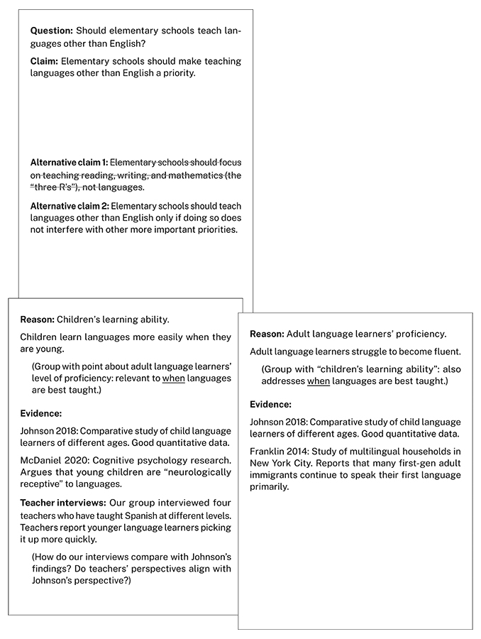

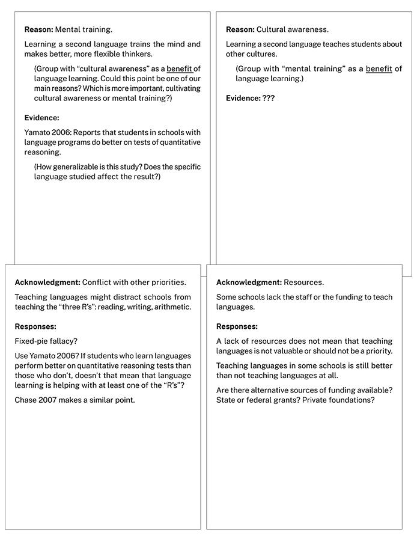

## 5.6 创建你的企业文化

## 5.6 Creating Your Ethos

最后总结一下：本章我们介绍了构成所有论证的五个要素——主张、理由、证据、论据、承认和回应。但论证还隐含着第六个要素：传统上……这被称为你的*信誉*。你的听众不仅会根据你的论证的理性构建来评判你的论点，还会根据你阐述论点时所展现的品格来评判。你是否像那种能够通过提供必要的背景信息来引导听众，为你的论点提供充分（既不过分也不过分）的论据，并能深思熟虑地从各个角度考虑问题的人？或者，你是否像……你是否只看到一种观点，而忽略甚至无视他人的观点？同样，在你的写作风格或表达方式中，你是否展现出对听众需求的体贴和对他们时间和注意力的尊重，还是显得生硬、傲慢或自说自话、晦涩难懂？（我们将在第15章和第16章探讨这些问题。）

A final word: In this chapter, we have introduced you to the five elements—claims, reasons, evidence, warrants, and acknowledgments and responses—from which all arguments are composed. But arguments have an implicit sixth element as well: what is traditionally called your *ethos*. Your audience will judge your arguments not just as intellectual constructions but also by the character you project when you make them. Do you seem to be the sort of person who brings the audience along by providing necessary background information, who offers sufficient (neither thin nor excessive) support for your claims, who thoughtfully considers issues from all sides? Or do you seem to be someone who sees only one point of view and dismisses or even ignores the views of others? Likewise, in your style of writing or your manner of presenting, do you show that you are sensitive to your audience’s needs and respectful of their time and attention, or do you come off as terse, arrogant, or self-indulgently opaque? (We’ll consider these concerns in chapters 15 and 16.)

认知超载：一些令人安心的话语

Cognitive Overload: Some Reassuring Words

大约在这个阶段，许多刚接触研究的学生开始感到不知所措。如果你也有这种感觉，那么要知道，你的焦虑与其说是源于智力和能力不足，不如说是源于经验匮乏。我们中的一位曾向法律写作老师解释，对于许多一年级法学生来说，新手身份让他们觉得自己写作能力差。讲座结束时，一位女士分享了她的经历：她曾是一位人类学教授，其发表的作品以清晰易懂的文笔而备受赞誉。后来，她转行进入法学院。她说，在最初的六个月里，她的写作混乱不堪，以至于她担心自己患上了某种退行性脑病。当然，她并没有患上这种病：她只是在经历我们大多数人都会经历的痛苦过渡期——当我们试图为一群我们更不了解的读者撰写自己并不完全理解的事物时，就会遇到这种困境。她欣慰地发现，自己对法律理解得越透彻，就越能写出优秀的法律文章。

At about this point, many students new to research begin to feel overwhelmed. If that’s how you are feeling, it may help to know that your anxieties have less to do with your intelligence and ability than with inexperience. One of us was explaining to teachers of legal writing how being a novice makes many first-year law students feel like incompetent writers. At the end of the talk, one woman reported that she had been a professor of anthropology whose published work was praised for the clarity of its writing. Then she switched careers and went to law school. She said that during her first six months, she wrote so incoherently that she feared she was suffering from a degenerative brain disease. Of course, she was not: she was going through the painful transition most of us experience when we try to write about matters we do not entirely understand for an audience we understand even less. She was relieved to find that the better she understood the law, the better she wrote about it.

如果你感到不知所措，可以从这个故事中获得安慰，就像一位读者给我们发邮件时所说的那样：

If you feel overwhelmed, you can take comfort in that story, as did one reader who e-mailed us this:

> 在*《研究的艺术》一书中，*你写到一位女性从人类学转行到法律，却突然发现自己无法清晰地写作。我做了五年平面设计助理教授后，最近转行到人类学，却突然发现写人类学论文简直难如登天。我当时甚至怀疑自己是不是得了什么脑部退行性疾病！读到那位人类学家转行做律师的故事时，我忍不住大笑起来。这让我感觉好多了。

> In *The Craft of Research* you write about a woman who switched from anthropology to law and suddenly found herself unable to write clearly. After being an assistant professor of graphic design for five years, I recently switched to anthropology and suddenly found that writing anthropology papers is like pulling teeth. I thought to myself that I might have a degenerative brain disorder! I laughed out loud when I read about the anthropologist who switched to law. It made me feel a bit better.

当你清晰、尊重地沟通，并预见并解决听众的疑问和顾虑时（这也是致谢和回应如此重要的原因之一），你就能赢得他们的信任，并让他们有充分的理由*与*你合作，共同开发和测试新想法。从长远来看，你在每次论证中展现出的风范会逐渐转化为你的声誉——这是每位研究人员都必须重视的——因为你的声誉是你所有论证中不可或缺的第六个要素。它回答了那个未说出口的问题：*我能信任你吗？*答案必须是*肯定的*。

When you communicate clearly and respectfully and anticipate and address your audience’s questions and concerns (this is another reason acknowledgments and responses are so important), you earn their confidence and give them good reason to work *with* you in developing and testing new ideas. In the long run, the ethos you project in individual arguments hardens into your reputation—something every researcher must care about—because your reputation is the tacit sixth element in every argument you make. It answers the unspoken question *Can I trust you?* That answer must be *Yes*.

▶ 小贴士：一个常见的错误——依赖你已知的知识

▶ Quick Tip: A Common Mistake—Falling Back on What You Know

如果你是一位经验不足的研究者，你可能会过于依赖熟悉的事物。你可能会过早地接受某个论断，甚至在进行大量研究之前就妄下断言，因为你“知道”自己能够证明它。但依赖这种确定性只会阻碍你进行最佳思考。作为一名研究者，意味着要允许自己被发现和洞见所震撼。因此，当你开始一个项目时，不要从你确信能够证明的论断入手，而是要从你想要探索和解决的问题入手。

If you are an inexperienced researcher, you may be tempted to rely too heavily on what feels familiar. You might embrace a claim too early, perhaps even before you have done much research, because you “know” you can prove it. But falling back on that kind of certainty will just keep you from doing your best thinking. Being a researcher means allowing yourself to be surprised by your discoveries and insights. So when you start a project, begin not with a claim you know you can prove but with a problem you want to explore and solve.

同样，当你初涉某个领域时，你可能会倾向于依赖那些你从教育或经验中熟悉的论证方式。如果你在文学课上学会了通过引用和分析原文来支撑论点，不要以为在强调“客观数据”的领域，比如生物学或实验心理学，也能做到这一点。另一方面，如果你作为生物学或心理学专业的学生，学会了通过收集确凿数据和进行统计分析来支撑论点，也不要以为在艺术史领域也能做到这一点。但这并不意味着你在一个领域学到的东西在另一个领域毫无用处。所有领域的论证都依赖于我们在此描述的要素。但你必须了解每个领域处理这些要素的独特方式，并保持足够的灵活性去适应，同时相信你所掌握的技能。

Likewise, when you are new to a field, you may be tempted to rely on ways of arguing that are familiar to you from your education or experience. If, in a literature class, you learned to support your claims by presenting and analyzing quotations, do not assume that you can do the same in fields that emphasize “objective data,” such as biology or experimental psychology. On the other hand, if as a biology or psychology major you learned to support your claims by gathering hard data and performing statistical analyses, do not assume that you can do the same in art history. This does not mean that what you learn in one class is useless in another. Arguments in all fields rely on the elements we describe here. But you have to learn what’s distinctive in the way a field handles those elements and be flexible enough to adapt, trusting the skills you’ve learned.

随着你对研究领域的深入了解，你可能会倾向于以另一种方式过度简化问题。一些初级研究人员一旦成功地提出某种论点，就会反复使用。他们对一种复杂性的掌握反而让他们忽略了另一种复杂性：他们没有意识到，如果研究领域活跃的话，那么它本身就充满了相互竞争的方法论、相互竞争的解决方案、相互竞争的目标和目的。不要落入这个陷阱。如果你能提出一种论点，不妨尝试其他论点：寻找替代方法，不仅要提出多种解决方案，还要提出多种支持这些方案的论证方式，并思考其他人是否会用不同的方法来处理你的问题。

And as you become more familiar with your field, you may be tempted to oversimplify in a different way. When some beginning researchers succeed at making one kind of argument, they just keep making it over and over. Their mastery of one kind of complexity keeps them from recognizing another: they fail to see that their field, if it is an active one, is marked by competing methodologies, competing solutions, competing goals and objectives. Don’t fall into this trap. If you can make one type of argument, try others: seek out alternative methods, formulate not only multiple solutions but multiple ways of supporting them, ask whether others would approach your problem differently.

# 6 提出索赔

# 6 Making Claims

在本章中，我们将讨论如何识别能够回答你的研究问题的主张类型，以及如何判断一个主张是否足够具体和重要，可以作为你论证的主要主张。

In this chapter, we discuss how to recognize the kind of claim that answers your research question and how to tell if a claim is specific and significant enough to serve as the main claim of your argument.

你需要对你的研究问题有一个初步的答案——也就是一个初步的论断——以此来集中精力寻找数据或信息，作为你研究论证的证据。在完善这个论断的过程中，你还必须确保它足够具体，具有可辩驳性，并且足够重要，值得论证。问问自己以下三个问题：

You need a provisional answer to your research question—that is, a provisional claim—to focus your search for data or information to use as evidence in your research argument. As you refine that claim, you must also be sure it is specific enough to be arguable and significant enough to need arguing for. Ask yourself three questions:

1. 1. 我应该提出什么样的索赔？
2. 1. What kind of claim should I make?
3. 2. 它是否足够具体，可以提出支持它的论点？
4. 2. Is it specific enough to suggest an argument for it?
5. 3. 我的听众会认为这件事重要到需要论证吗？
6. 3. Will my audience think it is significant enough to need an argument supporting it?

当你能够回答这三个问题时，你就可以开始构建你的论点了。

When you can answer those three questions, you’re ready to assemble your argument.

## 6.1 确定您应该提出的索赔类型

## 6.1 Determining the Kind of Claim You Should Make

你提出的问题类型决定了你提出的主张类型以及你需要用何种论证来支持它。正如我们在第二章中看到的，学术研究者通常提出的不是*实际*问题，而是*概念性问题，*这类问题的解决要求人们理解*而非*采取行动。

The kind of problem you pose determines the kind of claim you make and the kind of argument you need to support it. As we saw in chapter 2, academic researchers usually pose not *practical* problems but *conceptual* ones, the kind whose solution asks someone not to *act* but to *understand*.

我们也可以通过观察主张来做出类似的区分，因为它们可以回答一系列问题：*某事物或某种情况是否存在？如果存在，我们应该如何描述它？它是如何变成这样的？* *方式是什么？是好是坏？可以或应该如何应对？*前四个问题的答案是概念性主张。第五个问题的答案是实践性主张。您可以提出的主张将属于以下一个或多个类别：

We can make a similar distinction when it comes to claims by noticing that they can address a range of questions: *Does a thing or a situation exist? If so, how should we characterize it? How did it get this* *way? Is it good or bad? What can or should be done about it?* Answers to the first four of these questions are conceptual claims. Answers to the fifth are practical claims. The claims you can make will fall into one (or more) of the following classes:

概念性主张

CONCEPTUAL CLAIMS

- ▪ 关于事实或存在的主张：
  > 1. 中国和印度的花生产量合计占世界总产量的一半以上。
  > 2. ▪ 定义和分类的主张：
  > 3. 花生脱壳机是一种专门用于在花生烤熟后将其去壳的机器。
  > 4. 花生是豆类，不是坚果。
  > 5. ▪ 因果关系主张：
  > 6. 对花生高度过敏的人，即使只是触摸花生，也可能引发严重的过敏反应。
  > 7. ▪ 评估或鉴定的主张：
  > 8. 花生真是太好吃了。
- ▪ Claims of fact or existence:
  > 1. Together, China and India grow more than half of the world’s peanuts.
  > 2. ▪ Claims of definition and classification:
  > 3. A peanut sheller is a specialized machine used to shell peanuts after they are roasted.
  > 4. Peanuts are legumes, not nuts.
  > 5. ▪ Claims of cause and consequence:
  > 6. Just touching a peanut can provoke severe reactions in those who are highly allergic to them.
  > 7. ▪ Claims of evaluation or appraisal:
  > 8. Peanuts are absolutely delicious.
- 实际应用
- PRACTICAL CLAIMS
- ▪ 诉讼或政策索赔：
  > 1. 联邦政府应降低贸易壁垒以增加花生出口。
- ▪ Claims of action or policy:
  > 1. The federal government should lower trade barriers to increase peanut exports.

对于事实或存在性的主张，你必须提供证据证明某种情况确实如你所描述的那样。定义或分类的主张依赖于对相似性或差异性的推理，这种推理将一个实体归入某个更广泛的类别，或将其与其他实体区分开来。因果关系的主张将一系列事实联系起来，以表明某种情况确实（或并非）由另一种情况导致或引发。评价或评估的主张依赖于判断标准来证明其合理性。为什么某件事物是好是坏（或者比另一件事物更好或更差）。这些都是概念性的论断。

For claims of fact or existence, you must provide evidence that a situation is, in fact, as you characterize it. Claims of definition or classification depend on reasoning about similarities or differences that assigns an entity to some broader class or distinguishes it from other entities. Claims of cause or consequence connect sets of facts to show that some situation does (or doesn’t) follow from or lead to another. Claims of evaluation or appraisal depend on criteria of judgment to justify why something is good or bad (or better or worse than something else). These are all conceptual claims.

第五类主张是行动或政策主张，属于实践性主张，通常建立在先前的概念性主张之上：一个概念性主张定义问题或证明问题的存在，另一个概念性主张指出问题的原因，还有一个概念性主张解释你提出的方案如何解决问题。在论证一项实践性主张时，你可能需要解释以下内容：

The fifth type, a claim of action or policy, is a practical claim and usually rests on prior conceptual claims: one that defines the problem or demonstrates that a problem exists, another that identifies its causes, and still another that explains how doing what you propose will fix it. When arguing for a practical claim, you may need to explain the following:

- ▪ 为什么你的解决方案是可行的；如何用合理的时间和精力来实现它。
- ▪ Why your solution is feasible; how it can be implemented with reasonable time and effort.
- ▪ 为什么实施成本会低于解决问题的成本。
- ▪ Why it will cost less to implement than the cost of the problem.
- ▪ 为什么它不会造成比它所解决的问题更大的问题。
- ▪ Why it will not create a bigger problem than the one it solves.
- ▪ 为什么它比其他替代方案更好。
- ▪ Why it is better than alternative solutions.

如果你的听众期待这些子论点，而你却没有提出，他们可能会完全否定你的论点。最后，不要为了强调某个概念性主张的重要性而强加一个实际行动，至少在文章开头不要这样做。如果你想提出一个概念性主张的实际应用，应该在论证的结尾，也就是论文或演讲的结论部分。在那里，你可以把它作为一个值得考虑的行动提出，而无需展开论证（我们将在第14章再次讨论这一点）。

If your audience expects these sub-arguments and you don’t make them, your audience may reject your whole argument. Finally, don’t inflate the importance of a conceptual claim by tacking on a practical action, at least not early on. If you want to suggest a practical application of your conceptual claim, do so at the end of your argument, in the conclusion to your paper or presentation. There, you can offer it as an action worth considering without having to develop a case for it (we return to this point in chapter 14).

## 6.2 评估您的索赔

## 6.2 Evaluating Your Claim

我们无法告诉你如何找到一个好的诉求，但我们可以向你展示好的诉求是什么样的，以及如何评估你已有的诉求。最重要的是，你的诉求应该既具体又重要。

We can’t tell you how to find a good claim, but we can show you what good claims look like and how to evaluate the one you have. Above all, your claim should be both specific and significant.

### 6.2.1 明确你的诉求

### 6.2.1 Make Your Claim Specific

模糊的主张会导致模糊的论证。你的主张越具体，就越有助于你构建论证。比较以下两个主张：

Vague claims lead to vague arguments. The more specific your claim, the more it helps you plan your argument. Compare these two claims:

> 远程办公对社会有害。

> 远程办公会减少公共交通的客流量，并削弱市中心零售商和餐馆的自然客户群，从而威胁城市中心的社会结构。

> Remote work is detrimental to society.

> Remote work threatens the social fabric of urban centers by reducing ridership on public transportation and eroding the natural customer base for downtown retailers and restaurants.

第一种说法过于笼统，我们几乎无法预知接下来的内容。第二种说法则包含一系列具体概念，为研究者提供思路或主题，以便在接下来的论证中展开。这种具体性预示着论证可能的发展方向。

The first is so vague that we have little idea about what’s to come. The second includes a set of specific concepts that give the researcher ideas or themes to develop in the argument that follows. The claim’s specificity signals how the argument is likely to proceed.

### 6.2.2 使您的主张具有实质性意义

### 6.2.2 Make Your Claim Significant

在关注论断的具体性之后，受众最关注的是其*重要性，他们衡量重要性*的标准是：论断要求他们改变多少固有观念。虽然我们无法量化重要性，但可以粗略估计：如果*受众接受某个论断，他们需要改变多少固有信念？这些信念又有多么根深蒂固？*最重要的论断要求受众改变他们最坚定的信念（因此，他们会抵制这类论断）。

After the specificity of a claim, an audience looks most closely at its *significance*, a quality they measure by how much it asks them to change what they think. While we can’t quantify significance, we can roughly estimate it: *If an audience accepts a claim, how many beliefs must they change? And how foundational are those beliefs?* The most significant claims ask an audience to change their most strongly held beliefs (and they will resist such claims accordingly).

研究界有时认为，如果一项研究成果仅仅提供了关于某个感兴趣主题的新信息，那么它就具有重要意义：

Research communities sometimes consider a claim significant if it simply offers new information on a topic of interest:

> 本文介绍六部十三世纪用拉丁文写成的威尔士语语法著作。这些语法著作是近期才被发现的，也是同类著作中仅存的几部。它们有助于我们更好地了解中世纪时期语法著作的丰富多样性。

> I describe here six thirteenth-century Latin grammars of the Welsh language. Found just recently, these grammars are the only examples of their kind. They help us better appreciate the range of grammars written in the medieval period.

（回想一下引言[ I.4.1 ]中提到的华夫饼爱好者协会的成员们，他们只是想通过一些有趣的事实来消遣。）

(Recall the members of that Waffle Lovers Society from the introduction [I.4.1], who just wanted to be entertained by some interesting facts.)

但是，研究界更重视那些不仅提供新信息，而且*利用*这些信息来解决看似令人困惑、不一致或其他问题的研究成果：

But research communities value claims more highly when they not only offer new information but *use* that information to settle what seems puzzling, inconsistent, or otherwise problematic:

> 长期以来，关于消费者信心波动如何影响股市一直存在争论，但新的统计工具表明，两者之间几乎没有关系……

> There has been a long debate about how fluctuations in consumer confidence affect the stock market, but new statistical tools suggest little relationship between . . .

*而且，当某些主张*颠覆看似早已尘埃落定时，他们会给予最高的重视：

And they value claims most highly when they *upset* what seems long settled:

> 现代物理学长期以来一直坚信光速在任何时间、任何地点、任何条件下都是恒定的，但新的数据表明，事实可能并非如此。

> It has long been an article of faith in modern physics that the speed of light is constant everywhere at all times, under all conditions, but new data suggest it might not be.

这样的说法会遭到众多物理学家的反对，因为如果这是真的，那就意味着物理学家不仅要改变对光速的看法，还要改变对许多其他事情的看法。

A claim like that would be contested by legions of physicists because if true, it would mean that physicists would have to change their minds not just about the speed of light but about lots of other things as well.

强调你的论点重要性的一个简单方法是承认它挑战了当前的认知（参见第9章）。关于远程工作的第二个论点已经足够具体，但可能仍然显得片面。因此，可以通过添加一个以“*虽然”、“*尽管*”*或*“即便*”等词语或短语开头的限定性从句来“充实”它：

One simple way to signal the significance of your claim is to acknowledge the current understanding it challenges (see chapter 9). That second claim about remote work is specific enough, but it might still seem one-sided. So “thicken” it by introducing it with a qualifying clause beginning with a word or phrase like *although*, *while*, or *even though*:

> **虽然远程办公给公司和员工带来了许多好处，但**它也威胁到城市中心的社会结构，因为它减少了公共交通的客流量，并削弱了市中心零售商和餐馆的自然客户群。

> **Although remote work offers many benefits to companies and employees,** it also threatens the social fabric of urban centers by reducing ridership on public transportation and eroding the natural customer base for downtown retailers and restaurants.

*你可以使用以“虽然”或*类似词语开头的引导性从句来承认三种不同的观点：

You can use an introductory clause beginning with *although* or a similar word to acknowledge three kinds of alternative views:

- ▪ 你的听众所相信但你的论点挑战的是：
  > 1. 尽管许多人认为远程办公几乎没有任何负面影响……
  > 2. ▪ 与你的观点相冲突的观点：
  > 3. 尽管一些较早的研究表明，远程办公并不会显著降低城市消费者的支出……
  > 4. ▪ 限制您索赔范围或保证金的条件：
  > 5. 尽管远程办公模式出现时间尚短，难以评估其对城市的长期影响……
- ▪ Something that your audience believes but your claim challenges:
  > 1. Although many assume that remote work has few if any negative consequences . . .
  > 2. ▪ A point of view that conflicts with yours:
  > 3. Although some older research suggests that remote work does not significantly reduce consumer spending in cities . . .
  > 4. ▪ A condition that limits the scope or confidence of your claim:
  > 5. Although it is difficult to gauge the long-term effects of remote work on cities because it is so new . . .

如果你的听众可能会想到这些限定条件，那就首先承认它们的存在。这不仅表明你理解他们的观点，也承诺会在论证过程中回应这些观点。

If your audience might think of those qualifications, acknowledge them first. You not only imply that you understand their views, but you commit yourself to responding to them in the course of your argument.

如果你是一位资深研究人员，你会通过你的研究成果对所在领域（例如学术界）的认知和研究方式产生的改变程度来衡量其重要性。很少有科学成就能像传统DNA双螺旋结构模型那样意义重大。这项发现归功于詹姆斯·沃森和弗朗西斯·克里克。它不仅改变了科学家们对遗传学的思考方式，还在生物学、数学、历史学等学科领域创造了新的研究问题和机遇。沃森和克里克清楚地知道他们想要寻找的是什么。为了构建他们的模型，他们借鉴并整合了许多其他科学家几十年来的研究成果，其中包括莫里斯·威尔金斯和罗莎琳德·富兰克林的关键经验数据（关于这种情况的伦理问题，请参见17.2 ）。

If you are an advanced researcher, you measure the significance of your claim by how much it changes what your community thinks and how it does its research. Few scientific accomplishments have been as significant as the model of the double-helix structure of DNA traditionally credited to James Watson and Francis Crick. Not only did it make scientists think about genetics differently, but it created new research questions and opportunities in disciplines from biology to mathematics to history. Watson and Crick knew what they were looking for. To arrive at their model, they built on and integrated research findings by many other scientists going back decades, including crucial empirical data belonging to Maurice Wilkins and Rosalind Franklin (see 17.2 for more about the ethics of this situation).

但重大发现往往出乎意料。我们的一位同事，人类学家法卢·恩戈姆（Fallou Ngom）在他已故父亲的遗物中发现了一份用类似阿拉伯文字书写的文字，读起来像是西非语言沃洛夫语。恩戈姆感到困惑：虽然他在塞内加尔长大，但他从未听说过这种文字系统；事实上，他一直以为他的父亲根本不识字。出于好奇，他开始寻找其他类似的文字，结果发现到处都有。从西方学术的角度来看，他发现的是阿贾米文字（'Ajamī），一种源自阿拉伯文字并用于书写多种西非语言的文字系统。恩戈姆的发现颠覆了长期以来以欧洲为中心的观念，即许多西非社会都是文盲，而事实上，它们拥有可以追溯到几个世纪前的丰富文字文化。这一发现也为研究开辟了新的视野。

But significant discoveries also come by surprise. One of our colleagues, the anthropologist Fallou Ngom, found among his deceased father’s papers a piece of writing in an Arabic-like script that read like the West African language Wolof. Ngom was puzzled: although he had been raised in Senegal, he was unaware that such a writing system existed; in fact, he had thought that his father couldn’t write at all. Curious, he began looking for other examples of such writing and found it everywhere. What he discovered (from the perspective of Western scholarship) was ‘Ajamī, a writing system adapted from Arabic used to write a host of West African languages. Ngom’s discovery upended the long-established Eurocentric belief that many West African societies were illiterate when in fact they have rich written cultures going back centuries. And in so doing, it opened up new horizons for research.

这些故事展现了发现与专业知识之间复杂的关系：沃森和克里克利用他们的研究群体的工作成果解决了他们最重要的问题之一；恩戈姆在西方历史学和人类学学科方面的专业知识（他在法国和美国的大学接受了研究训练）使他能够从他父亲的论文中看到这些学科的重要性。

These stories show the complex relationship between discovery and expertise: Watson and Crick drew on the work of their research community to solve one of its most important problems; Ngom’s expertise in the Western disciplines of history and anthropology (he received his training as a researcher at French and American universities) allowed him to see the importance for those disciplines of that note in his father’s papers.

你不必提出惊世骇俗的论断才能对研究界做出有益的贡献。即使是微小的发现，如果能够挑战现有知识或提出新的问题，也可能意义重大（参见第一章）。例如，如果你发现马丁·路德·金在高中时期写过一篇关于某位哲学家的论文，历史学家就会仔细研究金后来的著作，寻找这种影响的痕迹。

You don’t have to offer a sweeping claim to make a useful contribution to a research community. Even small findings can be significant if they challenge current knowledge or raise new questions (see chapter 1). If, for example, you discovered that Martin Luther King Jr. wrote a high school paper on some philosopher, historians would comb King’s later writings for traces of that influence.

当然，如果你是一名学生或某个领域的新研究人员，你可能无法提出挑战专家观点的论断（或者无法识别出专家的观点）。当你发现这类论断时，可以先进行核实。但你仍然可以通过将你的论断置于你自身以及你的班级或同伴的知识和思维背景下进行思考，来体验为研究群体提出论证的意义。想象一下，听众都是和你一样的人。在你开始研究之前，*你是怎么想的？你的论断在多大程度上改变了**你*现在的想法？*你*现在理解了哪些以前不理解的东西？这是准备回答任何研究者都可能面临的最重要问题的最佳方式：不是“*我为什么要相信这个？”*，而是“*我为什么要关心这个？”*（参见 I.4.3、2.5 和 9.1）。

Of course, if you are a student or a new researcher in a field, you may not be able to make claims that challenge the experts (or to recognize such claims when you find them). But you can still experience what it means to make arguments for a research community by considering your claims in the context of your own knowledge and thinking, and that of your class or peers. Imagine an audience made up of people like yourself. What did *you* think before you began your research? How much has your claim changed what *you* now think? What do *you* understand now that you didn’t before? That’s the best way to prepare to answer the most important question any researcher can face: not *Why should I believe this?* but *Why should I care?* (See I.4.3, 2.5, and 9.1.)

## 6.3 提升信誉度的合格声明

## 6.3 Qualifying Claims to Enhance Your Credibility

一些新晋研究者认为，他们的论断越有力，就越可信。然而，傲慢的自信最会损害你的信誉。看似矛盾的是，谦逊地承认自身论证的局限性，反而能增强论证的说服力和可信度。当你认可并回应听众的观点时，就能赢得他们的信任，表明你不仅理解了他们的立场，而且认真考虑了他们的立场（参见第九章）。但如果你随后提出过于夸张的论断，就会失去这份信任。因此，要限定论断的范围和确定性，使其仅限于你的论证能够支持的内容。

Some new researchers think their claims are most credible when they are stated most forcefully. But nothing damages your ethos more than arrogant certainty. As paradoxical as it seems, you make your argument stronger and more credible by modestly acknowledging its limits. You gain the trust of your audience when you acknowledge and respond to their views, showing that you have not only understood but considered their positions (see chapter 9). But you can lose that trust if you then make claims that overreach. Limit your claims to what your argument can actually support by qualifying their scope and certainty.

### 6.3.1 承认限制条件

### 6.3.1 Acknowledge Limiting Conditions

每项索赔都有限制条件：

Every claim has limiting conditions:

> **我们预计，如果目前的保护措施继续实施**，切萨皮克湾的蓝蟹数量将继续增长。

> **根据现有经济数据，**全球经济衰退的可能性似乎不大。

> **根据目前的气候模型，**地球温度最早可能在 2030 年代中期比工业化前水平升高 2 摄氏度。

> We expect the blue crab population in the Chesapeake Bay to continue expanding, **assuming today’s conservation measures remain in place.**

> **Based on available economic data,** a global recession appears unlikely.

> **According to current climate models,** the earth could warm to two degrees Celsius over pre-industrial levels as soon as the mid-2030s.

因此，只需提及听众可能想到的例子即可。科学家很少承认他们的论断取决于仪器的精度，因为这种局限性适用于所有科学测量。但经济学家经常承认其论断的局限性，因为他们的预测会受到不断变化的情况的影响。因为他们想表明需要关注哪些条件。在下一个例子中，作者提及限制条件，使得论点能够得到更完整、更准确的阐述：

So mention only those that your audience might plausibly think of. Scientists rarely acknowledge that their claims depend on the accuracy of their instruments because that limitation applies to every scientific measurement. But economists often acknowledge limits on their claims because their predictions are subject to changing conditions and because they want to signal what conditions to watch for. In this next example, the writer’s mention of limiting conditions allows for a fuller and more accurate statement of the claim:

> 如今，富兰克林·罗斯福广受尊敬，但在他第二个任期末期，**至少在美国社会的某些群体中，他的支持率却很低**<sub>。</sub>例如，报纸抨击他宣扬社会主义，认为这是现代政府陷入困境的标志。1938年，中西部地区70%的报纸指责他想让政府管理银行系统……有些人持不同观点，包括尼科尔森（1983，1992）和威金斯（1973），他们都提供了一些轶事，<sub>表明</sub>但这些说法仅仅基于那些有意将罗斯福神化的人的记忆。<sub>除非</sub> **能够证明批评罗斯福的报纸受到特殊利益集团的控制，否则这种**<sub>说法</sub>存在局限性，即这些报纸<sub>的攻击</sub>表明民众对罗斯福的总统任期存在严重的不满。

> Today Franklin D. Roosevelt is widely revered, but toward the end of his second term, he was quite unpopular, **at least among certain segments of American society**.<sub>claim</sub> Newspapers, for example, attacked him for promoting socialism, a sign that a modern administration is in trouble. In 1938, 70 percent of Midwest newspapers accused him of wanting the government to manage the banking system. . . . Some have argued otherwise, including Nicholson (1983, 1992) and Wiggins (1973), both of whom offer anecdotal reports that Roosevelt was always in high regard,<sub>acknowledgment</sub> but these reports are supported only by the memories of those who had an interest in deifying FDR.<sub>response</sub> **Unless it can be shown that the newspapers critical of Roosevelt were controlled by special interests**,<sub>limitation on claim</sub> their attacks demonstrate significant popular dissatisfaction with Roosevelt’s presidency.<sub>restatement of claim</sub>

### 6.3.2 利用对冲来限制确定性

### 6.3.2 Use Hedges to Limit Certainty

我们很少能绝对肯定地陈述自己的观点。谨慎的作者会用一些词语和短语来限定他们的确定性，这些词语和短语被称为*“缓和语”*。

Only rarely can we state our claims with absolute certainty. Careful writers qualify their certainty with words and phrases called *hedges*.

沃森和克里克明白他们的 DNA 模型具有巨大的意义，但当他们宣布这一模型时，他们仍然对自己的说法有所保留（保留意见以粗体显示；引言部分已精简）：

Watson and Crick understood the tremendous significance of their model of DNA, but when they announced it, they still hedged their claims (hedges are boldfaced; the introduction is condensed):

> 我们**希望提出一种**脱氧核糖核酸（DNA）盐的结构（注：此处不*明确指出具体结构）。……鲍林和科里已经提出了核酸的结构。……***我们认为，**该结构存在两个不足之处：(1)**我们认为**， X射线衍射图谱所显示的物质是盐，而非游离酸。……(2)**部分**范德华距离**似乎**过小。（JD Watson 和 FHC Crick，《核酸的分子结构》）

> We **wish to suggest a** [note: not *state the*] structure for the salt of deoxyribose nucleic acid (D.N.A.). . . . A structure for nucleic acid has already been proposed by Pauling and Corey. . . . **In our opinion,** this structure is unsatisfactory for two reasons: (1) **We believe** that the material which gives the X-ray diagrams is the salt, not the free acid. . . . (2) **Some** of the van der Waals distances **appear** to be too small. (J. D. Watson and F. H. C. Crick, “Molecular Structure of Nucleic Acids”)

去掉这些限定语，这些句子会更简洁，但也更具攻击性。请将谨慎的段落与这个更强硬的版本进行比较（这种攻击性很大程度上源于缺乏*限定*）：

Without the hedges, these sentences would be more concise but also more aggressive. Compare that cautious passage with this more forceful version (much of the aggressive tone comes from the *lack* of qualification):

> We **announce** here **the** structure for the salt of deoxyribose nucleic acid (D.N.A.). . . . A structure for nucleic acid has already been proposed by Pauling and Corey. . . . Their structure **is** unsatisfactory for two reasons: (1) The material which gives their X-ray diagrams is the salt, not the free acid. . . . (2) Their van der Waals distances **are** too small.

在大多数领域，听众对使用*“所有”*、*“没有人”*、*“每个*” 、*“总是**”、“*从不”等词语表达的绝对确定性持怀疑态度，但如果你使用过多的模棱两可的措辞，又会显得畏首畏尾。不同的研究群体使用模棱两可的程度各不相同，找到合适的平衡点需要经验积累。因此，观察你所在领域的专家是如何运用模棱两可的措辞来论证观点的，并效仿他们的做法。

In most fields, audiences distrust pat certainty expressed in words like *all*, *no one*, *every*, *always*, *never*, and so on, but if you hedge too much, you will seem timid. Different research communities use hedges to different degrees, and finding the right balance is a matter of experience. So notice how experts in your field hedge their arguments and do likewise.

▶ 小贴士：让你的索赔可质疑

▶ Quick Tip: Make Your Claim Contestable

你可以通过询问是否有人会费心反驳来衡量你的观点是否具有潜在意义。如果没有人反驳，那么你的观点可能就不值得争论。以下是三个因不同原因而显得站不住脚的观点：

You can gauge the potential significance of your claim by asking whether anyone would bother to contest it. If not, then your claim may not be worth arguing. Here are three claims, which are weak for different reasons:

> 本报告总结了近期关于蜜蜂消失的研究成果。

> 巴拉克·奥巴马是美国第一位黑人总统。

> 在莎士比亚的《哈姆雷特》中，哈姆雷特并不是一个重要人物。

> This report summarizes recent research on the disappearance of bees.

> Barack Obama was the first Black president of the United States.

> Hamlet is not an important character in Shakespeare’s *Hamlet*.

要评估这些说法是否值得反驳，请考虑它们的反面：

To assess whether these claims are worth contesting, consider their opposites:

> 本报告并未总结近期关于蜜蜂消失的研究成果。

> 巴拉克·奥巴马并非美国第一位黑人总统。

> 哈姆雷特是莎士比亚戏剧《哈姆雷特》中的一个重要人物。

> This report does not summarize recent research on the disappearance of bees.

> Barack Obama was not the first Black president of the United States.

> Hamlet is an important character in Shakespeare’s *Hamlet*.

第一个论断仅仅是对报告主题的陈述。它的反面完全是无稽之谈。（准确地说，它是一个事实陈述，但事实是关于报告本身，而不是关于蜜蜂。）第二个论断（也是一个事实陈述）很容易验证。它的反面显然是错误的。第三个论断（一个评价性论断）或许看似有力，但它的反面显而易见，无需赘言。莎士比亚将他的戏剧命名为《*丹麦王子哈姆雷特的悲剧*》想必是有原因的。因此，这些论断都不值得争论——大概吧。

That first claim is merely an assertion of the report’s topic. Its opposite is just nonsensical. (To be precise, it is a claim of fact, but the fact is about the report, not about the bees.) The second (also a claim of fact) is easily verifiable. Its opposite is demonstrably false. The third (a claim of evaluation) may seem strong, but its opposite is so obvious that it goes without saying. Shakespeare presumably titled his play *The Tragedy of Hamlet, Prince of Denmark* for a reason. So none of these claims are worth arguing—probably.

该测试并非万无一失，一些伟大的思想家成功地反驳了看似不言而喻的说法，就像哥白尼那样，他当时愚蠢地断言——或者至少在当时看来是这样——*太阳不是绕着地球转的*。

The test isn’t foolproof, and some great thinkers have successfully contradicted apparently self-evident claims, as Copernicus did when he asserted foolishly—or so it seemed at the time—that *the sun does not go around the earth*.

# 7. 汇集理由和证据

# 7 Assembling Reasons and Evidence

本章我们将讨论两种论证方式：理由和证据。我们将向您展示如何区分二者，如何运用理由组织论证，以及如何评估证据的质量。

In this chapter, we discuss two kinds of support for a claim: reasons and evidence. We show you how to distinguish between the two, how to use reasons to organize your argument, and how to evaluate the quality of your evidence.

听众首先关注论证的核心：论点及其支撑。他们会特别关注论点的理由，以此判断其合理性，并考察理由的顺序，以此判断其逻辑性。如果他们认为这些理由合情合理，就会查看你提供的证据。如果他们不相信这些证据，就会否定这些理由，进而否定你的论点。

Audiences look first for the core of an argument: a claim and its support. They look particularly at its set of reasons to judge its plausibility and their order to judge its logic. If they think those reasons make sense, they will look at the evidence you present to back them up. If they don’t believe the evidence, they’ll reject the reasons and, with them, your claim.

因此，在构建论点时，你必须提供一套合情合理的理由，并以清晰、逻辑的顺序排列，且这些理由必须基于听众能够接受的证据。本章将向你展示如何做到这一点。

So as you assemble your argument, you must offer a plausible set of reasons in a clear, logical order, based on evidence your audience will accept. This chapter shows you how to do that.

## 7.1 运用理由来规划你的论点

## 7.1 Using Reasons to Plan Your Argument

When you order your reasons, you build a logical structure for your argument. Earlier, we recommended that you plan your argument using a *storyboard* (see 5.5). If you do, you can use it to test your argument’s logic or flow. Looking at the cards or pages in your storyboard, read the reasons, not the details, to see if their order makes sense. If it doesn’t, try different arrangements until it does. At this point, you are planning and developing only your argument, not your paper, report, or presentation. When you turn from your argument itself to figuring out how best to communicate it to others, you may need to make further adjustments. We’ll say more about drafting and delivering arguments in part IV.

## 7.2 区分证据与理由

## 7.2 Distinguishing Evidence from Reasons

一旦你将理由按合理的顺序排列好，务必确保你有足够的证据来支持每一个理由。证据就是你用来支撑理由的信息。问题在于，你无权决定证据是否充分，而是由你的听众来决定。要构成证据，陈述必须包含听众不太可能质疑的内容，至少在论证过程中是如此。但如果他们质疑，你认为确凿的证据在他们看来就只是另一个理由而已。请看以下论证：

Once you’ve arranged your reasons in a plausible order, be sure you have sufficient evidence to support each one. Your evidence is the information you use to back up your reasons. The problem is you don’t get to decide whether your evidence is sufficient; your audience does. To count as evidence, a statement must report something they can be expected not to question, at least for the purposes of the argument. But if they do question it, what you think is hard evidence becomes for them only another reason. Consider this argument:

> 美国高等教育必须遏制不断上涨的学费<sub>，</sub>因为大学学费正成为低收入学生进入中产阶级的一大障碍。<sub>理由是，</sub> <sub>如今</sub>**许多学生大学毕业时都背负着沉重的债务。**

> American higher education must curb escalating tuition costs<sub>claim</sub> because the price of college is becoming an impediment to lower-income students entering the professional middle class.<sub>reason</sub> **Today many students leave college with a crushing debt burden.**<sub>evidence</sub>

最后一句话以作者认为确凿的“事实”作为论据。但我们仍然可以质疑：*这只是一个概括性的说法。有什么确凿的数据来支撑“众多学生”或“沉重的债务负担”？*当我们提出这样的论断时，我们并非将其视为证据，而是将其视为一个次要理由，它本身也必须建立在证据之上。为了让我们信服，作者需要补充类似这样的内容：

That last sentence offers as evidence a statement its writers take to be a hard “fact.” But we could still question it: *That’s just a generalization. What hard numbers do you have to back up “many students” or “crushing debt burden”?* When we do, we treat that statement not as evidence but as a secondary reason that must rest on evidence of its own. To satisfy us, the writers would have to add something like this:

> 2020-2021学年，公立四年制大学43%的学生和私立四年制大学超过75%的学生背负联邦助学贷款，毕业生的平均债务超过3万美元<sub>。</sub>

> In 2020–21, 43 percent of students at public four-year colleges and over 75 percent of students at private four-year institutions held federal student loans, and the average debt of borrowers at graduation was over $30,000.<sub>evidence</sub>

如果我们*真的*心存疑虑，我们可以再次追问：*这些数据有什么依据？是什么能证明这种情况是一场危机？*如果是这样，作者就必须提供更确凿的数据，将这些数据细化，以证明债务对应届毕业生的影响。如果他们有原始数据，就可以展示出来。如果他们的数据来自二手资料，就可以注明出处。但即便如此，这些数据仍然可能受到质疑：*你们是如何收集数据的？我们凭什么相信你们的数据来源可靠？*原则上，这类问题可以一直问下去，但我们希望理性的读者在某个时刻能够停止追问——否则我们谁也无法做出任何有意义的结论。你无需提出任何论点。你的责任是提供到目前为止的证据。

If we were *really* skeptical, we could again ask, *What backs up those numbers? What justifies the claim that this situation is a crisis?* If so, the writers would have to provide still harder data, breaking down those numbers to document the consequences of debt for recent graduates. If they have it, they could show the raw data. If they drew those facts from a secondary source, they could cite the source. But even then, those facts could be questioned: *How did you collect your data? Why should we believe your source is reliable?* Such questions can, in principle, be asked forever, but at some point, we expect reasonable audiences to stop—or none of us would be able to make any arguments at all. Your responsibility is to offer evidence up to that point.

我们关于证据的基础隐喻

Our Foundational Metaphors for Evidence

当我们谈论证据时，通常会使用一些基础性的比喻：好的证据是*坚实的*、*可靠的*，是我们*构建论证的**基石*；而坏的证据则是*脆弱的*、薄弱的*或*不完整的*。这样的*语言容易让读者误以为证据是独立于任何人的解读和判断之外的客观存在。但事实上，数据总是由收集和使用它们作为证据的人构建和塑造的。在构建论证的过程中，请记住，只有当你的听众愿意接受你的证据时，它才能*真正起到*证据的作用，至少在目前是这样。

When we talk about evidence, we typically use foundational metaphors: good evidence is *solid* or *hard*, *the bedrock foundation* on which we *build* arguments. Bad evidence is *flimsy*, *weak*, or *thin*. Language like that encourages readers to think of evidence as a reality independent of anyone’s interpretation and judgment of it. But data are always constructed and shaped by those who collect and use them as evidence. As you build your argument, keep in mind that your evidence will *count* as evidence only if your audience is willing to accept it, at least for the moment.

## 7.3 确定你需要哪种类型的证据

## 7.3 Determining the Kind of Evidence You Need

你提出的论点类型将决定你需要何种理由来支撑它，以及你需要提供何种证据来佐证该理由。不同领域的学者往往依赖于各自特有的证据类型——经济学家和化学家可能更倾向于经验数据和统计模型；人类学家和社会学家可能依赖访谈和民族志；文学学者和历史学家可能需要文本或口述资料的引文——学习如何在某个领域进行研究，不仅意味着理解该领域的问题和挑战，还意味着学习如何找到或生成该领域论证所需的证据。但是，没有任何一个领域“拥有”某种特定类型的证据，或者仅仅依赖于任何单一类型的证据，尤其是在当今跨学科研究如此受重视的时代。

The kind of claim you make will determine the kind of reason you need to support it and the kind of evidence you need to present to back up that reason. Researchers in different fields tend to rely on characteristic sorts of evidence—economists and chemists might prefer empirical data and statistical models; anthropologists and sociologists might rely on interviews and ethnographies; literary scholars and historians might want quotations from textual or oral sources—and learning how to do research in a field means not just understanding its problems and questions but also learning how to find or produce the kinds of evidence its arguments require. But no field “owns” a particular sort of evidence or relies solely on any single kind, especially today, when interdisciplinary research is so prized.

因此，在构思论点时，既要考虑听众重视哪些类型的证据，也要考虑你需要哪些类型的证据来支持你的特定论点。以下是两个听起来相似但需要不同类型理由和证据的论点：

So as you plan your argument, consider both the sorts of evidence your audience will value and the kind of evidence you need to support any particular reason. Here are two claims that sound similar but need different kinds of reasons and evidence:

> 在*《母语者》*中，李昌来有力地展现了第一代移民子女所经历的双重意识。

> 在*《母语者》一书中*，李昌来准确地捕捉到了20世纪后期纽约市的种族政治。

> In *Native Speaker*, Chang-rae Lee powerfully represents the double consciousness experienced by the children of first-generation immigrants.

> In *Native Speaker*, Change-rae Lee accurately captures the racialized politics of late twentieth-century New York City.

第一种方法需要引用小说原文；第二种方法则需要引用原文并辅以历史证据。你需要的证据类型将决定你的研究方向。

For the first, you would need quotations from the novel; for the second, you would need quotations coupled with historical evidence. The kind of evidence you need will influence the kind of research you do.

## 7.4 区分证据与报告

## 7.4 Distinguishing Evidence from Reports of It

现在出现了一个复杂情况：研究人员很少会在任何论文或演示文稿中直接引用*证据本身。*即使你收集了自己的数据，比如在田野里数兔子，或者采访刚从投票站出来的选民，你也只能*用*文字、数字、表格、图表、图片等等来提及或呈现*这些兔子和选民。例如，当检察官在法庭上说琼斯**犯有伪造商品罪，并列举了证据证明这*一点时，这位检察官可以拿出从琼斯车库里找到的假冒古驰手提包，甚至可以让陪审员亲手触摸。（当然，检察官和陪审员都必须相信作证说在那里发现手提包的警官。）但是，当检察官撰写案件摘要*时，手提包不能钉在纸上；它只能被提及或描述。*

Now a complication: Researchers rarely include in any paper or presentation *the evidence itself*. Even if you collect your own data, counting rabbits in a field or interviewing voters exiting from a polling station, you can only *refer to* or *represent* those rabbits and voters in words, numbers, tables, graphs, pictures, and so on. For example, when a prosecutor says in court, *Jones is guilty of counterfeiting goods, and here is the evidence to prove it*, that prosecutor can hold up a fake Gucci handbag recovered from Jones’s garage and even let jurors hold it in their own hands. (Of course, both the prosecutor and the jurors must believe the officer who testifies to finding it there in the first place.) But when the prosecutor *writes* a brief on the case, the handbag can’t be stapled to the page; it can only be referred to or described.

同样，研究人员也不能与受众分享“证据本身”。例如：

In the same way, researchers cannot share with their audiences “the evidence itself.” For example:

> 情绪在理性决策中扮演的角色比许多人想象的要大。<sub>事实上</sub>，如果没有大脑的情感中枢，我们就无法做出理性的决定。<sub>支持论点的理由1：</sub>一些大脑情感中枢受到物理损伤的人甚至无法做出最简单的决定。<sub>支持理由2：</sub>例如，以Y先生为例…… <sub>（证据报告）</sub>

> Emotions play a larger role in rationality than many think.<sub>claim</sub> In fact, without the emotional centers of the brain, we could not make rational decisions.<sub>reason 1 supporting claim</sub> Some people whose brains have sustained physical damage to their emotional centers cannot make the simplest decisions.<sub>reason 2 supporting reason 1</sub> For example, consider the case of Mr. Y, who . . .<sub>report of evidence</sub>

这种论点并没有提供脑损伤患者的真实案例作为证据；它只能报告对他们行为的观察结果、脑部扫描图像、反应时间表格等等。（事实上，我们更愿意阅读他人的报告，而不是自己进行脑部测试和解读功能磁共振成像扫描结果。）

That argument doesn’t offer as evidence real people with damaged brains; it can only report observations of their behavior, copies of their brain scans, tables of their reaction times, and so on. (In fact, we prefer to read reports of others than to have to test brains and read fMRI scans ourselves.)

我们知道证据和证据报告之间的区别。这或许听起来像是个不错的例子，但我们坚持强调这一点是为了突出一个重要的观点：证据很少独立存在或不言自明；它几乎总是被用来支持某种论点，并且会受到这种用途的影响。当你从某个来源获取数据或信息时，请记住，这些数据或信息已经被整理成某种形式，以服务于该来源的目的。同样地，当你将自己收集或发现的数据或信息作为证据提交时，请记住，你不可避免地会通过你的研究方法以及你选择的报告方式来塑造它，使其符合你的目的。事实上，甚至在你开始收集任何数据之前，你就必须决定要统计什么、如何对数据进行分类、如何排序，以及是以表格、柱状图还是图表的形式呈现。即使是照片和视频录像也反映了某种特定的观点。简而言之，事实既受到收集者的影响，也受到使用者意图的影响。

We know this distinction between evidence and reports of evidence must seem like a fine one, but we insist on it to emphasize an important point: Evidence rarely stands alone or speaks for itself; it is almost always used to support some reason, and it is shaped by that use. When you take data or information from a source, remember that it has been put into a form that serves that source’s ends. Likewise, when you present as evidence data or information you gathered or discovered yourself, remember that you inevitably shape it to your ends, through your research methods and how you choose to report it. In fact, even before you started collecting anything at all, you had to decide what to count, how to categorize the numbers, how to order them, whether to present them in the form of a table, bar chart, or graph. Even photographs and video recordings reflect a particular point of view. In short, facts are shaped by those who collect them and again by the intentions of those who use them.

这种报告的模糊性正是为什么阅读大量研究报告的人对证据的可靠性要求如此之高的原因。例如，如果你自己收集定量数据，他们会想知道你是如何收集的。如果你依赖引用，他们会期望这些引用来自一手资料，或者尽可能接近一手资料。而且，他们会要求提供完整的引文和参考文献。这样，如果他们愿意，就可以自行查阅你的资料来源。再次强调，你作为研究者的职业操守至关重要：你的读者希望确保他们能够信任从“外界”信息到他们所读内容的完整信息链，而他们所能获得的最佳保障就是你卓越的专业能力和正直的声誉。

This squishy quality of reports of reports is why people who read lots of research are so demanding about the reliability of evidence. For example, if you collect quantitative data yourself, they will want to know how you did it. If you depend on quotations, they will expect them to come from primary sources, or as close to primary sources as you can get. And they will want complete citations and a bibliography so that they could, if they chose to, look at your sources themselves. Again, your ethos as a researcher is important: your audience wants to know they can trust the complete chain of reports between what’s “out there” in the world and what they are reading, and the best guarantee that they can have is your reputation for competence and integrity.

三百年前和现在，相信证据

Trusting Evidence Three Hundred Years Ago and Now

在实验科学的早期，研究人员会在所谓的“见证人”面前进行实验。这些“见证人”是声誉卓著的科学家，他们观察实验是为了验证所报告证据的准确性。如今，研究人员不再依赖见证人。相反，每个研究领域都制定了标准化的证据收集和报告方法，以确保其可靠性（前提是研究人员诚实）。当你遵循所在领域的标准程序时，你就是在鼓励读者不加核实地接受你的证据。因此，在阅读二手资料时，要注意他们引用的证据类型和引用方式，然后照搬他们的做法。在社会学领域，要像社会学家那样行事。

In the early days of experimental science, researchers conducted experiments before what they called “witnesses,” reputable scientists who observed the experiments so that they could attest to the accuracy of the reported evidence. Researchers don’t rely on witnesses anymore. Instead, each area of study has standardized its methodologies for collecting and reporting evidence to ensure that it is reliable (assuming the researchers are honest). When you observe the standard procedures in your field, you encourage your audience to accept your evidence at your word, without needing to examine it themselves. So as you read secondary sources, note the kind of evidence they cite and how they cite it, then do likewise. When in sociology, do as sociologists do.

我们生活在一个信息爆炸的时代，其中很多信息的可靠性令人怀疑，而且很多信息并非出自真人之手，而是由计算机“机器人”制造，其目的在于操纵或欺骗我们。信任链条的最后一环就是你，因此务必谨慎选择你使用的数据来源和使用方式。

We live in an age awash in information, much of it of dubious reliability, and much of it created—increasingly not even by other people but by computerized “bots”—with the intent of manipulating or deceiving us. The last link in that chain of credibility is you, so be thoughtful about whose data you use and how you use them.

## 7.5 评估你的证据

## 7.5 Evaluating Your Evidence

一旦你了解了你的研究群体期望的证据类型，你就可以通过问自己五个问题来检验你的证据：*你的证据或你对证据的报告是否准确？是否足够精确？是否充分且具有代表性？是否权威？是否清晰易懂？*（我们将在第八章添加第六个标准：相关性。）这些问题涉及我们用来评估证据的标准，这些标准不仅适用于学术和专业研究，也适用于日常对话，甚至与孩子交谈。

Once you know the kind of evidence your research community expects, you can test your evidence by asking five questions: *Is your evidence, or your reports of it, accurate? Appropriately precise? Sufficient and representative? Authoritative? Clear and understandable?* (We’ll add a sixth criterion, relevance, in chapter 8.) These questions get at criteria we apply to evaluate evidence not just in academic and professional research but also in ordinary conversations, even with children.

孩子：我需要一个新的书包去上学。<sub>声称：</sub>你看，这个太小了。<sub>证据：</sub>

Child: I need a new backpack for school.<sub>claim</sub> Look. This one is too small.<sub>evidence</sub>

家长：你今年应该不会比去年带更多东西，而且以前也完全没问题。[*也就是说，你的证据可能相关，但我拒绝接受，因为它不准确，而且即使准确，“太少”也不够精确]*。

Parent: You shouldn’t have to carry much more stuff this year than you did last year, and it was perfectly fine before [*i.e., your evidence could be relevant, but I reject it because it is not accurate and because even if it were accurate, “too small” is not adequately precise*].

孩子：可是它太旧了，不能上学了。<sub>理由：</sub>你看它多脏啊——还有这个坏掉的拉链。<sub>证据：</sub>

Child: But it’s too worn-out for school.<sub>reason</sub> Look how dirty it is—and this broken zipper.<sub>evidence</sub>

家长：污渍可以洗掉，拉链只是卡住了。这不足以买个新书包[*也就是说，你说的可能没错，但仅仅是污渍和拉链卡住并不足以证明书包不适合上学*]。

Parent: The dirt will wash off, and the zipper is just stuck. That’s not enough to buy a new backpack [*i.e., you may be factually correct, but dirt and a stuck zipper alone are not sufficient evidence that the backpack is unfit for school*].

孩子：我背疼。<sub>原因：</sub>你看我身体多僵硬。<sub>证据：</sub>

Child: It hurts my back.<sub>reason</sub> Look at how stiff I am.<sub>evidence</sub>

家长：你刚才还好好的[*即，你提供的证据不具代表性]* 。

Parent: You were fine just a minute ago [*i.e., your evidence is not representative*].

孩子：大家都觉得我应该买个新的。<sub>理由：</sub>哈利这么说的。<sub>证据</sub>

Child: Everybody thinks I should get a new one.<sub>reason</sub> Harry said so.<sub>evidence</sub>

家长：哈利的意见在这个家里并不重要[*即，哈利可能说过那样的话，但他的意见并不具有权威性]* 。

Parent: Harry’s opinion doesn’t matter in this house [*i.e., Harry may have said that, but his opinions are not authoritative*].

孩子：它会弄坏我的电脑。<sub>理由：</sub>你看这个口袋是怎么缝的！<sub>证据：</sub>

Child: It’s going to break my computer.<sub>reason</sub> Look at how this pocket is stitched!<sub>evidence</sub>

家长：我完全看不出来（*即，缝合会导致电脑损坏这一点并不明显）*。

Parent: I don’t see that at all [*i.e., it’s not evident that the stitching will lead to a broken computer*].

在收集证据时，请先根据这些标准进行筛选，然后再将其添加到故事板中。

As you assemble your evidence, screen it for those criteria before you add it to your storyboard.

### 7.5.1 你的证据准确吗？

### 7.5.1 Is Your Evidence Accurate?

人们常常混淆准确度和精确度。准确度指的是你对证据的报告与证据本身的吻合程度。（如果其他人重新进行你的测量，他们会得到和你一样的数据吗？如果他们核对你引用的小说段落，他们会发现你偶尔抄写错误吗？）精确度指的是对同一数值进行重复测量后，各次测量结果之间的接近程度。（当你重复进行三次实验时，每次测量结果之间的接近程度如何？）两者都很重要。

People often confuse accuracy and precision. Accuracy refers to how closely your report of your evidence matches the evidence itself. (If someone else were to redo your measurements, would they get the same numbers you did? If they were to check your quotations from a novel, would they discover that you mistranscribed a word here and there?) Precision refers to how close repeated measurements of a value are to each other. (When you ran your experiment three times, how close were your measurements to each other?) Both are important.

研究论证的受众往往抱持怀疑态度，因此他们会将证据中的错误视为你整体不可靠的标志。无论你的研究论证依赖于在实验室、田野、档案馆收集的信息，还是来自图书馆或网络资源的信息，都应完整清晰地记录下来，并在论文或演示文稿中使用时仔细核对（参见第四章）。注重细节体现了你的严谨。

The audiences for research arguments are predisposed to be skeptical, so they regard mistakes in your evidence as signs of your broader unreliability. Whether your research argument depends on information collected in a lab, in the field, in an archive, or from sources you found in the library or online, record that information completely and clearly, then double-check it when you use it in your paper or presentation (see chapter 4). Getting the small things right demonstrates your carefulness.

*即使证据本身存疑，只要你承认其可靠性*，有时也可以使用。事实上，如果你指出一些看似支持你论点的证据，但随后又指出其不可靠，这反而会展现出你的谨慎、自省，从而赢得信任。

You can sometimes use even questionable evidence, *if you acknowledge its dubious quality*. In fact, if you point to evidence that seems to support your claim but then reject it as unreliable, you show yourself to be cautious, self-critical, and thus trustworthy.

### 7.5.2 你的证据是否足够精确？

### 7.5.2 Is Your Evidence Appropriately Precise?

听众也希望你以恰当的精确度陈述证据。如果你说话含糊其辞，他们就会心存疑虑。其目的并非承认合理的各种不确定性，而是为了掩盖含糊不清之处：

Audiences also want you to state your evidence with appropriate precision. They become wary when you hedge in ways that seem intended not to acknowledge legitimate uncertainties but to excuse vagueness:

> 美国林务局投入了**大量**资金来预防森林火灾，但发生大型**、****代价高昂的森林火灾的可能性仍然很高**。

> The Forest Service has spent **a great deal** of money to prevent forest fires, but there is still **a high probability** of **large, costly** ones.

多少钱才算*大手笔？**高概率*到底有多大——30 %？80%？什么才算大手笔*且*昂贵*？*注意诸如“一些”、 *“大多数*” 、 “*许多”*、“几乎*”、**“经常”*、“*通常*” 、*“一般*”等词语。*这些*词语可以恰当地缩小结论的范围，但如果研究人员没有认真核实数据，它们也可能造成误导。

How much money is *a great deal*? How probable is *a high probability*—30 percent? 80 percent? What counts as *large* and *costly*? Watch for words like *some*, *most*, *many*, *almost*, *often*, *usually*, *frequently*, *generally*, and so on. Such words can appropriately limit the breadth of a claim, but they can also fudge it if the researcher didn’t work hard enough to get the precise numbers.

然而，何为恰当的精确度，因领域而异。物理学家以纳秒的几分之一来测量夸克的寿命，因此可接受的误差范围微乎其微。历史学家在估算苏联何时走向不可避免的崩溃时，会以月为单位进行估计。古生物学家对新发现物种的年代测定，误差可能在数万年左右。按照各自领域的标准，这三种方法都算是恰当的精确度。（证据也可能过于精确。只有鲁莽的历史学家才会断言苏联在1987年8月18日下午2点13分走向不可避免的崩溃。）

What counts as appropriately precise, however, differs by field. A physicist measures the life of quarks in fractions of a nanosecond, so the tolerable margin of error is vanishingly small. A historian gauging when the Soviet Union reached the point of inevitable collapse would estimate it in months. A paleontologist might date a newly discovered species give or take tens of thousands of years. According to the standards of their fields, all three are appropriately precise. (Evidence can also be too precise. Only a foolhardy historian would assert that the Soviet Union reached its point of inevitable collapse at 2:13 p.m. on August 18, 1987.)

### 7.5.3 你的证据是否充分且具有代表性？

### 7.5.3 Is Your Evidence Sufficient and Representative?

初学者通常提供的证据太少。他们认为只需引用一句话、一个数字或一次个人经历就能证明某个论点（尽管有时只需要一条证据就足以*反驳它*）。例如：

Beginners typically offer too little evidence. They think they prove a claim with one quotation, one number, one personal experience (though sometimes only one bit of evidence is sufficient to *disprove* it). For example:

> 莎士比亚一定是位女权主义者，因为*《第十二夜》*和*《无事生非》中的女性角色*都非常自信。

> Shakespeare must have been a feminist because the women in *Twelfth Night* and *Much Ado about Nothing* are so self-confident.

观众需要更多信息才能接受如此重大的论断。

An audience needs more than that to accept such a significant claim.

即使你提供大量证据，你的听众仍然会期望这些证据能够*代表所有*可获取的证据类型。莎士比亚一两部戏剧中的女性角色并不能代表他笔下的所有女性角色，正如莎士比亚的作品并不能代表伊丽莎白时代的所有戏剧一样。当你的证据样本量很小时，听众尤其会保持警惕。从大量数据中，例如调查数据，得出结果。无论何时使用抽样数据，不仅数据必须*具有*代表性，而且还必须*证明*这一点。

Even if you offer lots of evidence, your audience will still expect it to be *representative* of the full range of variation in what’s available. The women in one or two Shakespearean plays do not represent all his women, any more than Shakespeare represents all Elizabethan drama. Audiences are especially wary when your evidence is a small sample from a large body of data, as in surveys. Whenever you use sampled data, not only must your data *be* representative, but you must *show* that it is.

证据有时会因*轶事性质而受到质疑。*轶事*是对个人经历或事件的*简短描述。轶事证据并非通过系统性的研究方法收集，而是随意地通过个人经验获得。它可能具有代表性，但也可能不具有代表性。当然，人们往往容易被故事打动，因此轶事证据有时比统计数据更具说服力。正是这些具有说服力的例子、完美的案例研究或例外证明规则的例子，使得以轶事为论据既有力又充满风险。

Evidence is sometimes questioned for being *anecdotal*. An *anecdote* is a short report of a personal experience or episode. Anecdotal evidence is evidence gathered not systematically by applying a research method but arbitrarily through personal experience. It might be representative but, then again, it might not. Of course, people tend to be moved by stories, so anecdotal evidence can sometimes be persuasive in ways that statistics are not. The very persuasiveness of the telling example, the perfect case study, or the exception that proves the rule makes argument by anecdote powerful but also risky.

与之相关的指控是“断章取义” *，*即只呈现那些支持某种理由和主张的证据，而忽略其他不相关的证据。这种指控对研究人员来说是最具破坏性的，因为它不仅意味着粗心大意，还意味着不诚实。为了避免这种指控，你必须证明你已经考虑了所有可用的证据。

A related charge is that of *cherry-picking*, of presenting only those bits of evidence that support a reason and claim and ignoring available pieces of evidence that don’t. This charge is one of the most devastating a researcher can face because it implies not just carelessness but dishonesty. To avoid it, you must show that you have considered all of the evidence available to you.

### 7.5.4 你的证据是否具有权威性？

### 7.5.4 Is Your Evidence Authoritative?

一般来说，研究人员会根据信息来源的严谨性和客观性来判断其权威程度。因此，不仅要考虑信息来源的*内容*，还要考虑其*类型*。例如，大多数科学家会接受美国疾病控制与预防中心（CDC）提供的病毒传播数据，即使考虑到其中可能存在误差（即便一些怀疑论者质疑CDC的客观性，并认为其指导意见受到政治因素的影响）。然而，很少有人会信任来自维基百科的同一主题的数据，或者在研究报告中引用维基百科，因为在他们所属的研究群体中，维基百科并不被视为权威来源。

In general, researchers assign degrees of authority to sources based on their reputation for rigor and objectivity. That’s why it’s important to consider not just *what* a source says but also *what kind* of source it is. For example, most scientists would accept data on the transmission of viruses obtained from the US Centers for Disease Control as credible, even allowing for the possibility of error (and even if some skeptics doubt the CDC’s objectivity and see its guidance as being tainted by politics). However, few would trust data on the same topic taken from Wikipedia—or cite Wikipedia in a research report—because in the research communities to which they belong, Wikipedia is not regarded as authoritative.

这个例子引出了一个重要的观点：在研究论证中，对信息来源权威性的判断通常是由研究群体而非个人做出的。这些判断以*同行评审流程为支撑，*在同行评审过程中，研究群体的成员会对研究成果进行审查。论点在发表之前，以及支持学术和科学研究并传播其成果的机构和组织的信誉，都取决于这些机构和组织的信誉：大学和大学出版社、像美国疾病控制与预防中心这样的政府组织，甚至拥有许多学术期刊和数据库的商业企业。

This example raises an important point: In research arguments, judgments about the authority of sources are typically made by research communities, not individuals. They are backed by processes of *peer review*, in which members of a research community vet research arguments before they are published, and by the credibility of the institutions and organizations that support scholarly and scientific research and propagate its results: universities and university presses, governmental organizations such as the CDC, even commercial enterprises such as those that own many academic journals and databases.

### 7.5.5 你的证据是否清晰易懂？

### 7.5.5 Is Your Evidence Clear and Understandable?

你的证据或许准确、精确、充分、具有代表性且权威，但如果听众觉得晦涩难懂，无法*理解*其如何支撑你的论点，那么你提供的证据就形同虚设。无论你提供的是引文、量化数据还是视觉证据，务必确保听众能够注意到你想让他们注意到的内容。

Your evidence may be accurate, precise, sufficient and representative, and authoritative, but if your audience finds it perplexing, if they can’t *understand* how it supports your argument, then you might as well have offered no evidence at all. Whether you are offering quotations, quantitative data, or visual evidence, be sure your audience will notice in it what you want them to notice.

例如，引文很少能“不言自明”；你需要解释和解读它们，以确保你的听众能够理解对你来说可能不言而喻的含义。这里，关于《哈姆雷特》的一个论断是基于以下引文的证据：

Quotations, for instance, rarely “speak for themselves”; you need to explain and interpret them to be sure your audience gets a connection that may be self-evident to you. Here, a claim about Hamlet is based on the evidence of the quotation that follows:

> 当哈姆雷特撞见叔叔克劳狄斯正在祈祷时，他表现出冷静的理性<sub>：</sub>

> 现在我可以动手杀了他吗？现在他正在祈祷。

> 现在我不会了。于是，我就去了天堂。

> 因此，我的仇终于报了……（哈姆雷特停顿片刻，沉思）

> 但是这个恶棍杀害了我的父亲，为此，

> 我，他唯一的儿子，也犯下了同样的罪行。

> 升入天堂。

> 为什么？这是雇佣和薪酬问题，不是报复。(3.3)<sub>证据报告</sub>

> When Hamlet comes upon his uncle, Claudius, at prayer, he demonstrates cool rationality:<sub>claim</sub>

> Now might I do it [kill him] pat, now ’a is a-praying,

> And now I’ll do’t. And so ’a goes to heaven,

> And so am I reveng’d. . . . [Hamlet pauses to think]

> [But this] villain kills my father, and for that,

> I, his sole son, do this same villain send

> To heaven.

> Why, this is hire and salary, not revenge. (3.3)<sub>report of evidence</sub>

但这段引文如何支持这一论点尚不明确，因为其中没有任何内容明确提及哈姆雷特的理性。相比之下，请比较以下内容：

But it’s not clear how that quotation supports the claim because nothing in it explicitly refers to Hamlet’s rationality. In contrast, compare this:

> 当哈姆雷特撞见叔叔克劳狄斯正在祈祷时，他表现出了冷静的理性。他<sub>冲动</sub> **地想要杀死克劳狄斯，但随即停下来思考——如果趁克劳狄斯祈祷时杀了他，他的灵魂就能升入天堂，但他想让克劳狄斯下地狱，所以他冷静地决定稍后再杀他：**<sub>这是出于理性。</sub>

> 现在我可以动手了吗（杀了他）？拍拍手……<sub>证据报告</sub>

> When Hamlet comes upon his uncle, Claudius, at prayer, he demonstrates cool rationality.<sub>claim</sub> **He impulsively wants to kill Claudius but pauses to reflect—if he kills Claudius while praying, he will send his soul to heaven, but he wants Claudius damned to hell, so he coolly decides to kill him later:**<sub>reason</sub>

> Now might I do it [kill him] pat, . . .<sub>report of evidence</sub>

现在我们明白其中的联系了。

Now we see the connection.

同样的原则也适用于呈现定量数据或可视化图像。以下是一家咨询公司向客户展示的案例。该客户是一家全球零售商，他们想知道其大销量门店和小销量门店哪家更有增长潜力。咨询公司的研究表明，虽然大销量门店目前的销售额更高，但小销量门店蕴藏着更好的增长机会。报告的初稿包含以下图表：

The same principle applies when you present quantitative data or visual images. Here’s an example from a consulting firm’s presentation to a client. The client, a global retailer, wanted to know whether its large-volume or small-volume stores had greater potential for growth. The consulting firm’s research showed that while the large-volume stores currently had more sales, its smaller-volume stores offered a better growth opportunity. The first version of the report included this chart:

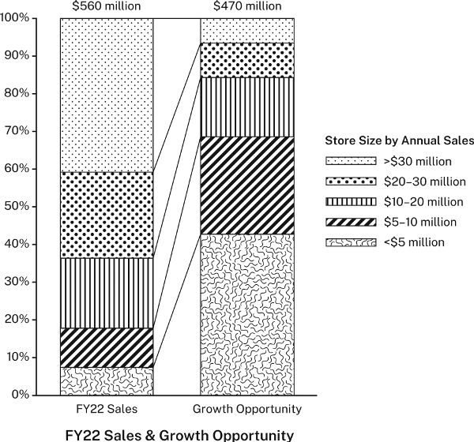

但这张图表掩盖了重点，因为它强调的是总销售额和总商机，而不是不同规模门店的相对销售额和商机。在报告的最终版本中，咨询公司将原图表拆分为两张，以便更好地进行比较：

But that chart obscures its point because it emphasizes total sales and total opportunity, not the relative sales and opportunity of different-sized stores. In the final version of the report, the consulting firm broke the original chart into two, to better show the comparison:

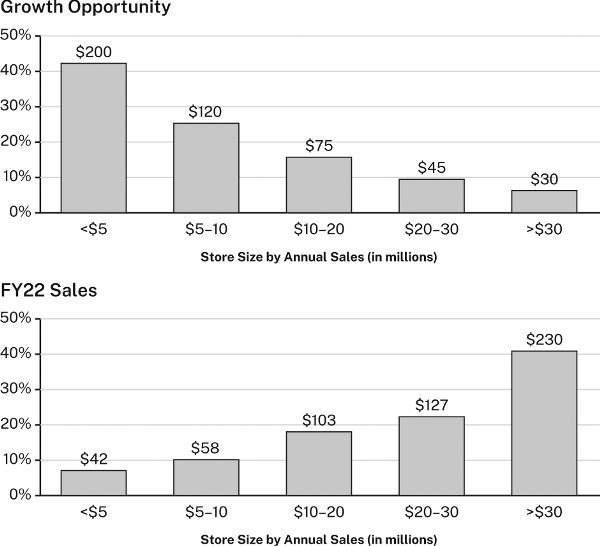

现在，由于这两个图表共享一个共同的水平轴，我们可以看到这种关系：随着商店规模的增加，即使 2022 财年的销售额上升，预期的增长机会也会下降。

Now, because both charts share a common horizontal axis, we can see the relationship: as store size increases, the anticipated growth opportunity goes down even though fiscal-year sales for 2022 go up.

图像也同样如此。如果观看者没有注意到研究者希望他们注意到的图像内容，他们可能就不会将该图像视为证据。因此，研究者有时会对图像进行增强处理，以突出或展现某些特征。但务必小心，不要让你的“增强”演变成捏造证据。这很容易导致错误的判断。

The same holds for images. If viewers don’t notice in an image what a researcher wants them to, they might not understand that image as evidence. For this reason, researchers sometimes enhance their images to highlight or bring out certain features. But be careful that your “enhancements” don’t amount to fabricating evidence. It can be a slippery slope.

▶ 小贴士：收集证据的同时评估证据质量

▶ Quick Tip: Assess Your Evidence as You Gather It

在第四章中，我们鼓励你们在笔记中积极运用各种资料，不仅要包含引文或书目信息，还要包含你们自己的想法和感受（参见4.3-4.5 ） 。这一点在记录可能用作证据的数据或信息时尤为重要，因为构成论证核心的三个要素——论点、理由和证据——中，只有证据并非由你们自己构建。记住，论点是你们*对自身观点的陈述*，理由是支持这些观点的陈述。但证据并非陈述（尽管你们可能会用陈述来呈现证据）；它是支撑其他陈述的数据或信息（参见5.2和7.2 ）。你们需要确保证据记录准确无误，同时也需要理解其价值和局限性。因此，在收集证据的过程中，就要开始评估它。思考一下你们对证据的信任程度以及可以如何利用它。记录你对证据可靠性的判断，你对证据的任何疑虑，甚至是它所暗示的论证思路（*你为什么选择记录*这些*数字*或*引文？）* 。让本章的问题引导你（参见7.5 ）。在收集证据的过程中对其进行评估，至少在三个方面对你有所帮助：首先，它可以避免你陷入机械地记录越来越多的数据和信息的陷阱，这实际上是一种拖延（如果你一直记笔记，就会推迟撰写论文的繁重工作）。其次，它能让你之后更严谨地评估证据，因为你已经有了最初的反应。最后，它能让你尽早思考最终要提出的论点。

In chapter 4, we encouraged you to engage sources actively in your notes, to include in them not just quotations or bibliographic information but your own thoughts and reactions (see 4.3–4.5). Doing that is especially important when you are recording data or information that you might use as evidence because of the three elements that make up your argument’s core—a claim, reasons, and evidence—your evidence is the only one that you don’t formulate yourself. Remember, your claims are *statements* of your ideas, and your reasons are statements that support them. But your evidence isn’t a statement (although you might make statements to report it); it’s the data or information on which those other statements are based (see 5.2 and 7.2). You need to know that it has been recorded accurately, but you also need to understand its value and limitations. So begin assessing it as you gather it. Consider how far you can trust it and what you might do with it. Note your sense of its reliability, any concerns you have about it, even lines of argument it suggests (*Why did you choose to record* those *numbers or* that *quotation?*). Let the questions in this chapter guide you (see 7.5). Assessing your evidence as you gather it will help you in at least three ways: It will protect you from the trap of mechanically recording more and more and more data and information, which can be a kind of procrastination (if you keep taking notes, you can put off the hard work of drafting). It will enable you to evaluate your evidence more rigorously later because you’ll have your initial reactions to it. And it will get you thinking early about the argument you will eventually make.

# 8份逮捕令

# 8 Warrants

论据是连接理由和论点的一般原则。本章将解释何时以及如何使用论据。所有研究论证都包含论据，正如它们包含论点、理由和证据一样。但与这些核心要素不同，论据通常不被明确指出。一般来说，只有当听众不陈述论据就无法理解你的论点，或者你预期听众会质疑你的推理时，才应该陈述论据。

Warrants are general principles that connect reasons to claims. This chapter explains when and how to use them. All research arguments have warrants, just as they have claims, reasons, and evidence. But unlike these core elements, warrants are often left unstated. In general, you should state your warrants only when your audience will not understand your argument otherwise or when you expect your audience to challenge your reasoning.

请考虑以下论点：

Consider this argument:

> Japan faces a declining standard of living<sub>claim</sub> because its fertility rate is only 1.3 and falling.<sub>reason</sub>

有人回应道：

Someone responds:

> 你说的日本生育率确实如此，但我不太明白为什么这意味着日本的生活水平会下降。这怎么可能呢？

> Well, you’re right about Japan’s fertility rate, but I don’t see why that means Japan’s standard of living will decline. How does that follow?

如果你要提出这样的论点，你会如何回答？提供日本生育率的证据并无帮助，因为问题不在于理由本身的真假，而在于理由如何支撑你的论点。这个问题触及了论证的第四个也是最抽象的要素：论证的依据。论证依据是连接理由和论点的普遍原则。它们至关重要，因为它们解释或授权了使论证成为可能的推理过程。理解论证依据对你来说很重要，因为你可能不仅会面临关于理由真假的问题，还会面临关于其*相关性的*问题。在这种情况下，你需要能够解释的不仅是*你的*理由和证据是什么，还有*它们*为什么支持你的论点（这可能比听起来要难）。归根结底，每一个关于论证依据的问题都是关于你信念基础的问题：它挑战你认识到，你的论证之所以有意义，仅仅是因为你接受了某些原则（你的信念）。（保证书）并承认，当持有不同原则的人考虑你的理由和证据时，他们可能会得出与你不同的结论，或者根本无法得出任何结论。

If you were making that argument, how would you answer? Offering evidence of Japan’s fertility rate wouldn’t help because the question is not about the truth of the reason itself but about how it supports the claim. The question gets at the fourth and most abstract element of an argument: its warrants. Warrants are general principles that connect reasons to claims. They are essential because they explain or authorize the reasoning that makes arguments possible. They are important for you to understand because you may face questions not just about the truth of a reason but about its *relevance* as well. In that case, you need to be able to explain not just *what* your reasons and evidence are, but *why* they support your claim (which can be harder than it sounds). Every question about your warrants is, ultimately, a question about the basis of your beliefs: it challenges you to recognize that your argument makes sense only because you accept certain principles (your warrants) and to acknowledge that when others who hold different principles consider your reasons and evidence, they may arrive at different conclusions than you did or at no conclusions at all.

幸运的是，大多数时候，我们无需进行这种哲学思考。这是因为我们的大部分权利都来自我们参与的社群，不仅包括我们的研究和专业社群，还包括我们的社交和家庭群体、政治和宗教信仰，甚至我们的文化。

Luckily, most of the time, we are spared from such philosophizing. That’s because most of our warrants are given to us by the communities in which we participate, including not just our research and professional communities but also our social and familial groups, political and religious affiliations, and even our cultures.

实际上，基本原则是：只有当你的听众持有不同的论据、不陈述论据就无法理解你的推理，或者可能质疑你的推理时，才需要陈述你的论据。当为某个领域的专家辩护时，你可以省略大部分论据，因为这些专家通常会认为这些论据是理所当然的。

As a practical matter, the basic principle is this: state your warrants only if your audience holds different ones, will not be able to understand your reasoning unless you do, or may challenge your reasoning. When making arguments for experts in a field, you can leave most of your warrants unstated because those experts will usually take them for granted.

## 8.1 日常推理中的论证

## 8.1 Warrants in Everyday Reasoning

虽然“论据”的概念很抽象，但我们却时时刻刻都在依赖它。当我们引用谚语来佐证自己的观点时，就能很容易地理解它的存在。这是因为谚语是人人都熟悉的文化论据。例如，有人会说：

While the concept of warrants is abstract, we rely on them all the time. We understand them easily enough when we offer proverbs to justify our reasoning. That’s because proverbs are cultural warrants that we all know. For example, someone says:

> 我听说联邦调查局一直在讯问市长的幕僚。<sub>原因：</sub>市长肯定牵涉到什么不正当的勾当<sub>。</sub>

> I hear the FBI has been questioning the mayor’s staff.<sub>reason</sub> The mayor must be involved in something crooked.<sub>claim</sub>

另一个人可能会反驳说：“*你说得对。联邦调查局确实讯问了市长的幕僚，但这又怎么能说明市长本人腐败呢？”*为了解释得出这个结论的逻辑，第一个人可能会引用一句谚语：“*无风不起浪”。*也就是说，当我们看到一些不祥之兆时，就可以推断出事情确实出了问题。

Another person might object, *You’re right. The FBI has been questioning the mayor’s staff, but why does that mean the mayor is crooked?* To explain the reasoning that led to that conclusion, the first person might offer the proverb, *Well, where there’s smoke, there’s fire.* That is, when we see a sign of something wrong, we can infer that something is in fact wrong.

推理过程如下。大多数谚语都包含两个截然不同的部分：情况（*无风*不起浪）及其后果（*……必有大事发生*）。如果某种情况通常蕴含某种后果，那么我们就可以依靠这种联系来推断具体案例。就“无风不起浪”这句谚语以及FBI和市长之间的事件而言，推理过程如下：

The reasoning works like this. Most proverbs have two distinct parts: a circumstance (*Where there’s smoke . . .*) and its consequence (*. . . there’s fire*). If a circumstance implies a consequence in general, then we can rely on that connection to license our inferences in specific instances. In the case of the proverb about smoke and fire and that situation with the FBI and the mayor, the reasoning looks like this:

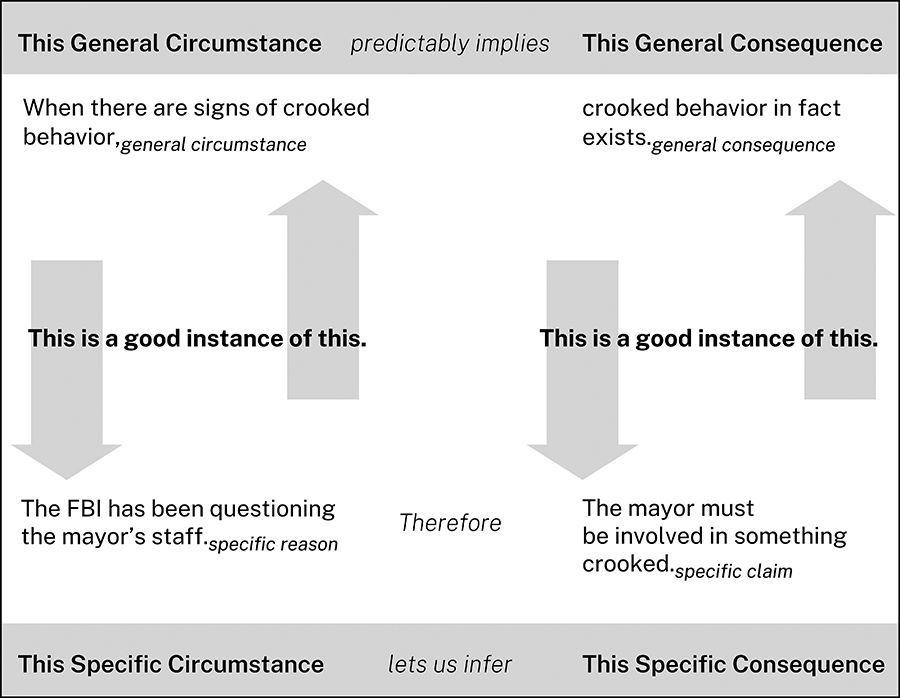

我们用谚语来佐证许多日常推理：因果关系（*欲速则不达*）；行为准则（*三思而后行*）；可靠的推断（*一燕不成夏*）。但谚语并非我们日常生活中唯一使用论据的例子。我们无处不在地使用论据：体育运动中（*防守赢得冠军）；*烹饪中（*只在月份名称中带有“r”的月份供应牡蛎）；*定义中（*质*数只能被它本身和1整除）；甚至在研究中（当*受众发现某个证据有误时，他们就会对其他证据产生怀疑）* 。

We use proverbs to justify many kinds of everyday reasoning: cause and effect (*Haste makes waste*); rules of behavior (*Look before you leap*); reliable inference (*One swallow does not a summer make*). But such proverbs are not our only examples of everyday warrants. We use warrants everywhere: in sports (*Defense wins championships*); in cooking (*Serve oysters only in months with an “r”*); in definitions (*A prime number can be divided only by itself and one*); even in research (*When an audience finds an error in one bit of evidence, they distrust the rest*).

## 8.2 研究论证中的证据

## 8.2 Warrants in Research Arguments

在研究人员和其他专业人士的专业论证中，论证工作方式完全相同，但在某些方面有所不同，这可能会使它们难以管理，特别是对于那些刚接触该领域的人来说。

In the specialized arguments of researchers and other professionals, warrants work in exactly the same way, but they differ in some respects that can make them difficult to manage, especially for those new to a field.

首先，研究论证中的依据并非总是我们普遍认同的常识；它们通常是特定研究领域特有的推理原则。新研究人员需要时间来掌握其研究领域的依据——事实上，这占据了很大一部分时间。学习像生物学家、历史学家、医生等等那样思考意味着什么。

First, the warrants in research arguments aren’t always commonplaces we share; they are often specialized principles of reasoning that belong to particular research communities. It just takes time for new researchers to grasp the warrants of their fields—in fact, that’s much of what it means to learn to think like a biologist, a historian, a physician, and so on.

其次，专家在与其他专家交流时很少明确说明自己的资质，因为他们可以理所当然地认为其他专家已经了解这些资质。（把显而易见的资质说出来可能会显得居高临下，或者更糟的是，会暴露所谓的专家其实根本不是专家。）

Second, experts rarely state their warrants explicitly when they address their fellow specialists because they can safely assume their fellow specialists already know them. (To state warrants that should be obvious could seem condescending or—worse—unmask a purported expert as no expert at all.)

虽然这种不明确列出既定论据的做法对研究界大有裨益，但识别出其中的论据也同样重要，这不仅对评估现有论证的人有帮助，对刚刚入门的新手也同样重要。假设现有证据支持该论证，生物学家会接受以下论点：

While this practice of leaving accepted warrants unstated serves research communities well, it is also useful to be able to identify warrants at work, both for those assessing arguments they’ve been offered and for novices just learning their fields. Assuming the available evidence supports the reason, biologists would accept this argument:

> <sub>有人声称</sub>，鲸鱼与河马的亲缘关系比与牛的亲缘关系更近，因为它与河马的DNA更相似。<sub>理由</sub>

> A whale is more closely related to a hippopotamus than to a cow<sub>claim</sub> because it shares more DNA with a hippopotamus.<sub>reason</sub>

没有哪个生物学家会问：*“是什么让DNA与亲缘关系的测定相关？”*因此，没有哪个生物学家在为其他生物学家撰写文章时会提供理由来回答这个问题。然而，如果一个非生物学家问了这个问题，生物学家就会给出其他生物学家习以为常的理由：

No biologist would ask, *What makes DNA relevant to measuring relationship?* So no biologist writing for fellow biologists would offer a warrant answering that question. If, however, a non-biologist asked that question, the biologist would answer with a warrant other biologists take for granted:

> When a species shares more DNA with one species than it does with another,<sub>circumstance</sub> we infer that it is more closely related to the first.<sub>consequence</sub>

当然，生物学家可能还需要解释这一论证的依据。关键在于：论证是否被明确提出，不仅取决于论点本身，还取决于受众。研究群体成员只有在与群体外人士交流或受到质疑时，才会阐述那些对其他成员而言显而易见的原则。

Of course, the biologist would probably then have to explain that warrant as well. The point is this: whether or not a warrant gets stated explicitly depends not only on the argument but also on the audience. Members of a research community state principles that are obvious to other members only when they communicate with those outside their community—or when challenged.

第三，研究群体所掌握的专业授权书通常以简略的方式表述，将背景和后果压缩开来。在大多数谚语中，这两部分是分开的：*无风**不起*<sub>浪。</sub> <sub>但我们</sub>也可以将这两部分压缩成一句简短的陈述：无风*不起浪。这*在谚语中很少见，但专家们却经常这样做。

Third, the specialized warrants belonging to research communities are often stated in ways that compress their circumstances and consequences. In most proverbs, these parts are distinct: *Where there’s smoke,*<sub>circumstance</sub> *there’s fire.*<sub>consequence</sub> But we can also compress those two parts into one short statement: *Smoke means fire*. That’s something we rarely do with proverbs but that experts do often:

> 共享的DNA是衡量物种间亲缘关系的指标。

> Shared DNA is the measure of the relationship between species.

这样表述，我们生物学家的论证并没有明确区分情况及其后果，但我们可以做到。为了清晰起见，我们将论证以最明确的形式表述：*当 X 发生时，则 Y 发生。*

Phrased this way, our biologist’s warrant doesn’t explicitly distinguish a circumstance from its consequence, but we can. For purposes of clarity, we’ll state warrants in their most explicit form: *When X, then Y.*

以下是关于日本经济前景的论点：

Here again is that argument about Japan’s economic future:

> Japan faces a declining standard of living<sub>claim</sub> because its fertility rate is only 1.3 and falling.<sub>reason</sub>

如果有人反对该理由似乎*与*论点无关，那么提出论点的人必须提供证据来证明这种联系的合理性：

If someone objects that the reason seems *irrelevant* to the claim, the person making the argument would have to offer a warrant to justify the connection:

> When a nation’s labor force shrinks,<sub>general circumstance</sub> its economic future is grim.<sub>general consequence</sub>

情况和结果都必须比具体的原因和主张更具普遍性。从视觉上看，这种逻辑如下所示：

Both the circumstance and consequence have to be more general than the specific reason and claim. Visually, that logic looks like this:

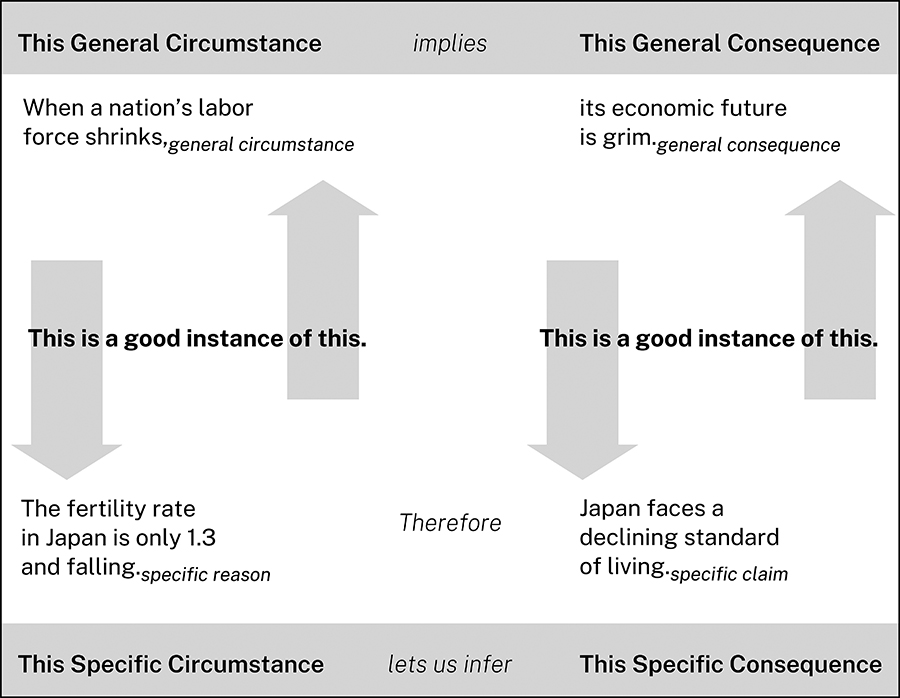

日常推理和专业推理的模式是一样的。

The pattern is the same in everyday and specialized reasoning.

## 8.3 测试授权

## 8.3 Testing Warrants

观众对证据的质疑方式是可以预见的。请看以下论点：

Audiences challenge warrants in predictable ways. Consider this argument:

> 十八世纪初的新英格兰，除了最富裕的农民之外，其他农民拥有钟表<sub>的</sub>可能性似乎不大，因为农民的遗嘱中很少提及钟表。<sub>理由</sub><sub>是</sub>，对1700年至1750年间马萨诸塞州四个县存档的124份此类遗嘱进行审查后发现，只有14%的遗嘱提到了任何类型的钟表。

> It seems unlikely that in early eighteenth-century New England, many farmers other than the most affluent owned a clock<sub>claim</sub> because clocks are rarely mentioned in farmers’ wills.<sub>reason</sub> A review of 124 such wills filed in four Massachusetts counties between 1700 and 1750 shows that only 14 percent mention a clock of any sort.<sub>report of evidence</sub>

这种说法很可能会受到那些信仰受到挑战的人的质疑。即使他们接受理由属实——即遗嘱中确实很少提及钟表——他们仍然可能会反对：*但我看不出这如何能作为认为很少有农民拥有钟表的理由。这无关紧要。*如果提出这种论点的历史学家预料到会有人反对，那么他可能会在提出论点时先说明反对的理由：

Such a claim is likely to be questioned by those whose beliefs it challenges. Even if they accept that the reason is true—that clocks were in fact rarely mentioned in wills—they may still object: *But I don’t see how that counts as a reason to believe that few farmers owned clocks. It’s irrelevant.* If a historian making this argument anticipated that objection, that historian might introduce it with its warrant:

> 十八世纪初的新英格兰，遗嘱会列出贵重的家居用品，因此，如果遗嘱中没有提及某件物品，则说明立<sub>遗嘱</sub>**人并不拥有该物品**。<sub>因此</sub>，似乎不太可能……

> In early eighteenth-century New England, wills listed valuable household objects, **so when a will fails to mention such an object, the testator did not own one**.<sub>warrant</sub> It therefore seems unlikely that . . .<sub>claim</sub>

需要注意的是，这个论点还依赖于第二个前提：适用于马萨诸塞州农民的情况也适用于新英格兰地区更广泛的农民群体。但如果历史学家认为这一点不会受到质疑，那么它就可以不被提及。

Note that this argument depends on a second warrant as well: that what’s true of farmers in Massachusetts is true of farmers in New England more broadly. But if the historian believes it won’t be questioned, it can go unstated.

一份成功的搜查令必须满足五个条件。也就是说，被搜查人员必须能够对以下问题回答“是”：

A successful warrant must meet five conditions. That is, an audience must be able to say “yes” to the following questions:

1. 1. 这个搜查令合理吗？
2. 1. Is that warrant reasonable?
3. 2. 是否足够有限？
4. 2. Is it sufficiently limited?
5. 3. 它是否优于任何竞争性认股权证？
6. 3. Is it superior to any competing warrants?
7. 4. 它是否适用于该领域？
8. 4. Is it appropriate to this field?
9. 5. 它是否能够涵盖理由和索赔？
10. 5. Is it able to cover the reason and claim?

### 8.3.1 你的搜查令合理吗？

### 8.3.1 Is Your Warrant Reasonable?

当受众能够接受其结果源于具体情况时，该论证就显得合理。如果你的受众一开始就不接受你的论证，那么你就必须说服他们接受它。将其视为自身论证中的一个主张，并由其自身的理由和证据加以支持：

A warrant seems reasonable when an audience can accept that its consequence follows from its circumstance. If your audience won’t accept your warrant on its face, then you have to convince them to accept it by treating it as a claim in its own argument, supported by its own reasons and evidence:

> 十八世纪初的新英格兰，遗嘱会列出贵重的家居用品，因此，如果遗嘱中没有提及某件物品，则表明立遗嘱人并不拥有该物品。<sub>迈尔斯</sub>和温恩（2018）的研究证实了这一点。<sub>他们</sub>对十八、十九世纪美国继承习俗的研究表明<sub>……</sub>

> In early eighteenth-century New England, wills listed valuable household objects, so when a will fails to mention such an object, the testator did not own one.<sub>warrant/claim</sub> Myles and Winn (2018) confirm that to be the case.<sub>reason</sub> Their study of inheritance practices in eighteenth- and nineteenth-century America shows that . . .<sub>evidence</sub>

### 8.3.2 您的授权是否足够有限？

### 8.3.2 Is Your Warrant Sufficiently Limited?

大多数搜查令只有在一定范围内才合理。例如，关于钟表所有权的搜查令就过于僵化，因为它似乎不允许任何例外情况：

Most warrants are reasonable only within certain limits. For example, the warrant about clock ownership is too rigid because it seems to allow no exceptions:

> 十八世纪初的新英格兰，遗嘱会列出贵重的家居用品，因此，如果遗嘱中没有提及某件物品，则表示立遗嘱人并不拥有该物品。

> In early eighteenth-century New England, wills listed valuable household objects, so when a will fails to mention such an object, the testator did not own one.

如果加上限定条件，或许会显得更合理一些：

It might seem more plausible if it were qualified:

> 在十八世纪初的新英格兰，遗嘱**通常**会列出**主人认为特别珍贵的家居用品，因此，**如果遗嘱中没有提及此类物品，则立遗嘱人**可能**没有该物品。

> In early eighteenth-century New England, wills **usually** listed household objects **considered especially valuable by their owners**, so when a will fails to mention such an object, the testator **probably** did not own one.

But once you start qualifying a warrant with words like *usually*, *probably*, and *especially*, you may then have to show that its exceptions do not exclude your reason and claim: *What frequency are* usually *and* probably*? Were clocks considered* especially *valuable?*

### 8.3.3 您的认股权证是否优于任何竞争认股权证？

### 8.3.3 Is Your Warrant Superior to Any Competing Warrants?

您可能认为您的搜查令合理且范围足够有限，但其他搜查令可能与之竞争或取代它。以下是两种相互竞争的搜查令，两者都可能被认为是合理的：

You may think your warrant is reasonable and sufficiently limited, but other warrants might compete with or supersede it. Here are two competing warrants, both arguably reasonable:

> **当人们认为某种医疗程序可能会对他们造成伤害时，他们有权拒绝。**泰勒认为新冠疫苗会导致心肌炎，因此他有权拒绝接种。

> **当医疗决策涉及公共卫生问题时，国家有权对其进行监管。**广泛接种新冠疫苗能使所有人更安全，因此国家可以强制政府雇员接种疫苗。

> **When people believe a medical procedure may harm them, they have a right to refuse it.** Taylor believes that the COVID-19 vaccine causes myocarditis, so he has a right to refuse it.

> **When medical decisions concern matters of public health, the state has a right to regulate them.** Widespread vaccination for COVID-19 makes everyone safer, so the state can compel government employees to receive it.

哪份搜查令应该生效？这需要争论。

Which warrant should prevail? That’s a matter for argument.

有时可以通过限制相互冲突的认股权证来调和它们：

You can sometimes reconcile competing warrants by limiting them:

> **当人们认为某种医疗程序可能会伤害自己时，他们有权拒绝，** 只要这种拒绝不会危及他人的健康**。**

> **当医疗决定涉及公共卫生问题时，国家有权对其进行监管，** 只要国家尽可能少地侵犯个人对其身体的控制权**。**

> **When people believe a medical procedure may harm them, they have a right to refuse it,** so long as that does not jeopardize the health of others**.**

> **When medical decisions concern matters of public health, the state has a right to regulate them,** so long as the state encroaches as little as possible on individuals’ right to control what happens to their bodies**.**

找到合适的平衡点，或者说找到任何平衡点，并非易事。事实上，所谓的“文化战争”争论（例如关于新冠疫苗接种要求的争论）之所以如此激烈且难以解决，是因为它们更多地关乎相互冲突的价值观和原则（即各自的理由），而非理由或证据。

Finding the right balance, or any balance at all, is not always easy. In fact, so-called “culture wars” arguments (like those over COVID-19 vaccine requirements) are often so heated and intractable because they are more about competing values and principles (that is to say, warrants) than about reasons or evidence.

### 8.3.4 您的授权书是否适用于此领域？

### 8.3.4 Is Your Warrant Appropriate to This Field?

你的论证理由或许合理、范围足够窄，也优于其他理由，但它仍然必须被认为适用于该论证所涉及的领域。法学生在学习法律时会痛苦地发现，许多日常论证理由在法律论证中毫无用处。大多数人在进入法学院时都持有这种常识性的观念：

Your warrant may be reasonable, sufficiently limited, and superior to others, but it still has to be accepted as appropriate to the field to which an argument contributes. Law students get a painful lesson in the law when they find that many everyday warrants have no place in legal arguments. Most start law school holding this commonsense belief:

> 当一个人受到不公正对待时，法律应当予以纠正。

> When a person is wronged, the law should correct it.

但法学生必须明白，法律依据可能凌驾于此类常识之上。例如：

But law students have to learn that legal warrants may supersede such commonsense ideas. For example:

> 即使是无意的，忽视法律义务的人也必须承担后果。

> When one ignores legal obligations, even inadvertently, one must suffer the consequences.

所以：

Therefore:

> 当老年房主忘记缴纳房产税时，其他人可以因拖欠税款而购买他们的房屋并将其驱逐。

> When elderly home owners forget to pay real estate taxes, others can buy their houses for back taxes and evict them.

法学生必须明白，从严格的法律意义上讲，正义不是他们认为合乎道德的结果，而是法律和法院支持的结果。

Law students must learn that justice, in a strictly legal sense, is not the outcome they believe to be ethical but the one that the law and the courts support.

### 8.3.5 您的保修单是否能够涵盖您的理由和索赔？

### 8.3.5 Is Your Warrant Able to Cover Your Reason and Claim?

最后，您必须确保您的理由和主张能够充分体现搜查令所涉的一般情况和一般后果。例如：

Finally, you must be sure that your reason and claim are good instances of your warrant’s general circumstance and general consequence. For example:

艾哈迈德：或许你应该开始用个效率应用，<sub>理由</sub><sub>是</sub>，你老是缺席我们的员工会议。

Ahmed: Maybe you should start using a productivity app,<sub>claim</sub> because you keep missing our staff meetings.<sub>reason</sub>

贝丝：你为什么觉得一款效率应用就能让我参加员工会议？

Beth: Why do you think a productivity app will get me to attend our staff meetings?

艾哈迈德：如果你更有条理，<sub>通常情况下，你</sub><sub>就</sub>更有可能记住你的约会。

Ahmed: If you’re more organized,<sub>general circumstance</sub> you’re more likely to remember your appointments.<sub>general consequence</sub>

贝丝：嗯，我缺席那些会议并不是因为我缺乏条理。

Beth: Well, I don’t skip those meetings because I’m unorganized.

贝丝反对的并非艾哈迈德的理由是假的，而是这个理由不符合搜查令的一般*情形**。*她并不否认缺席过那些员工会议；她只是否认缺席的原因是她做事没条理。（也许她只是觉得这些会议浪费时间。）在她看来，艾哈迈德的理由不在其搜查令的涵盖范围内，因此与本案*无关*。

Beth objects not that Ahmed’s reason is false but that it is not a valid *instance* of his warrant’s general *circumstance*. She doesn’t deny missing those staff meetings; she only denies that the reason she’s missing them is because she’s unorganized. (Maybe she just finds them a waste of time.) To her, Ahmed’s reason isn’t covered by his warrant and is therefore not *relevant*.

贝丝也可能回应说，使用效率应用会让她变得不那么有条理：

Beth might also have responded that using a productivity app would make her less organized:

贝丝：我一直都用日程本，所以我觉得应用程序对我没什么帮助。

Beth: I’ve always used a day planner, so I really don’t think an app would help me.

在这种情况下，她会反对艾哈迈德的说法不是搜查令*后果的一个很好的例子，*换句话说，这*并非*从他的理由中得出的结论：即使她没有条理，生产力应用程序也帮不了她。

In that case, she would be objecting that Ahmed’s claim isn’t a good instance of the warrant’s *consequence*, in other words, that it doesn’t *follow* from his reason: even if she were unorganized, a productivity app wouldn’t help her.

Most real-world arguments are like this one, in which what “counts” as an instance of a warrant’s general circumstance or what follows as a specific consequence is a matter of debate and negotiation rather than one of uncontested definition. Ahmed and Beth might reasonably disagree about what makes a person “unorganized” as they never would about what makes a geometrical figure a triangle. This is yet another reason arguments about warrants lead to further arguments and, ideally, to better understanding.

## 8.4 何时申请搜查令

## 8.4 Knowing When to State a Warrant

任何领域的论证都依赖于无数的推理原则，但其中大多数都深深植根于研究者的隐性知识中，或已被普遍接受，以至于常常被忽略甚至忽视。然而，在以下三种情况下，你可能需要明确地陈述论证依据：

Arguments in any field depend on countless principles of reasoning, but most of these are so embedded in researchers’ tacit knowledge or so generally accepted that they go unnoted and even unnoticed. There are three occasions, however, when you may have to state a warrant explicitly:

1. 1.**你的听众并非你的专业领域。**当你向不具备你专业知识的听众阐述观点时，你可能需要解释你所在领域的专家是如何得出结论并支持其论点的，尤其是当这些推理方式不寻常时。
2. 1. **You are addressing an audience outside your field.** When you make an argument for an audience that does not share your expertise, you may need to explain how experts in your field draw conclusions and support their claims, especially if these ways of reasoning are unusual.
3. 2.**你运用了在你所在领域较为新颖或存在争议的推理原则。**当你依赖非常规的推理原则时，你的论点至少会受到部分人的质疑。因此，你需要阐明并论证你的论点，以消除这些质疑。你可以引用你所在领域中其他受人尊敬的学者也运用过类似的推理原则。如果无法做到这一点，你需要提出自己的论证来捍卫你的推理。
4. 2. **You use a principle of reasoning that is new or controversial in your field.** When you rely on unconventional principles of reasoning, you can anticipate that your argument will be received at least by some with skepticism. So defuse that skepticism by stating your warrant and justifying it. Refer to respected figures in your field who also use it. If you can’t do that, make an argument of your own defending your reasoning.
5. 3.**你提出的观点可能会引起一些人的抵触，因为他们不愿接受这个事实。**在这种情况下，一个好的策略是先提出一个你希望他们能够接受的证据，*然后*再 阐述理由并声称你怀疑他们会抵触。他们或许仍然不喜欢你的说法，但至少你会让他们意识到你的观点并非毫无道理。例如：
   > 1. 我们应该接受人类活动是气候变化的主要原因<sub>这一说法</sub>，因为几乎所有气候科学家都持有这种观点<sub>。</sub>

   > 听众可能会抵制这种说法，因为它威胁到他们其他根深蒂固的信念。面对这样的听众，研究人员可以尝试提供他们应该能够接受的论据，以此鼓励他们至少考虑这种说法：

   你不说的话，反映了你是怎样的人。

   当你陈述并论证一些听众可能不熟悉的推理原则时，你对听众表现出了礼貌。但如果你对那些本应向不了解相关知识的听众阐明的论证保持沉默，你也同样做出了一种强硬（尽管不那么友好）的姿态。无论如何，论证都会显著影响听众对你通过论证所展现的信誉的感知。
   > 1. **当绝大多数合格的专家得出相同的结论时，我们大概可以相信这个结论。因此，**<sub>我们</sub>应该接受人类活动是气候变化的主要原因<sub>这一说法，</sub>因为几乎所有气候科学家都持有这种<sub>观点</sub>

   > 当听众认可某个理由合理、某个理由真实，并且该理由和主张都符合该理由所针对的一般情况和后果时，他们至少在逻辑上就有义务考虑该*主张。如果他们不考虑，任何理性的论证都难以改变他们的想法。*
6. 3. **You make a claim that some will resist because they just don’t want it to be true.** In this case, a good strategy is to offer a warrant you hope they will accept *before* you lay out a reason and claim you suspect they will resist. They may not like the claim any better, but you will at least encourage them to see that it is not unreasonable. For example:
   > 1. We should accept that human actions are largely responsible for climate change<sub>claim</sub> because virtually all climate scientists hold that view.<sub>reason</sub>

   > An audience may resist that claim because it threatens other strong convictions they hold. A researcher confronting such an audience might encourage them at least to consider that claim by giving them a warrant that they should be able to accept:

   What You Don’t Say Says Who You Are

   You treat your audience courteously when you state and support warrants to explain principles of reasoning that they may not recognize. But you make an equally strong (though less friendly) gesture when you keep silent about warrants you should state for an audience not in the know. One way or the other, warrants significantly affect how audiences perceive the ethos you project through your arguments.
   > 1. **When an overwhelming majority of competent experts arrive at the same conclusion, we can probably trust it.**<sub>warrant</sub> We should therefore accept that human actions are largely responsible for climate change<sub>claim</sub> because virtually all climate scientists hold that view.<sub>reason</sub>

   > When an audience accepts that a warrant is reasonable, that a reason is true, and that the reason and claim are good instances of the warrant’s general circumstance and consequence, then they are logically obliged at least to *consider* the claim. If they don’t, no rational argument is likely to change their minds.

## 8.5 使用搜查令检验你的论点

## 8.5 Using Warrants to Test Your Argument

你可以通过尝试想象一个支持该论点的理由来检验其合理性。以下是一个有缺陷的论点：

You can test the soundness of an argument by trying to imagine a warrant for it. Here’s a flawed argument:

> 如今12至16岁的青少年比上一代同龄人更容易出现心理健康问题。布朗（2021）<sub>的研究</sub>表明，自2010年以来，儿童焦虑和抑郁的发生率有所上升……<sub>由此可见</sub><sub>，</sub>社交媒体正在对儿童的心理健康产生不利影响。

> Children aged 12–16 today are significantly more prone to mental health problems than were their counterparts from a generation ago.<sub>reason</sub> Brown (2021) has shown that since 2010, the incidence of anxiety and depression in children has risen by . . .<sub>evidence</sub> We must conclude that social media is having a detrimental effect on children’s mental health.<sub>claim</sub>

为了理解问题所在，我们可以尝试设想一种论证，将既定理由——儿童心理健康问题日益增多——与社交媒体至少在一定程度上造成这一增长的说法联系起来。这种说法看似合情合理，甚至可能属实，但却缺乏令人满意的论证（即，一种能够将……与上述论点联系起来的论证）。满足8.3 )中列出的五个标准，可以*将该*具体理由与*该*具体主张联系起来。该理由需要类似于这样：

To understand what’s wrong here, we can try to imagine a warrant that would connect the stated reason—children’s mental health problems are increasing—to the claim that social media is at least in part responsible for that increase. That claim seems commonsensical and may even be true, but there is no satisfying warrant (that is, one that satisfies the five criteria noted in 8.3) that can connect *that* specific reason to *that* specific claim. The warrant would need to be something like this:

> 当儿童心理健康状况恶化时，社交<sub>媒体</sub><sub>往往难辞其咎。</sub>

> When children’s mental health is affected for the worse,<sub>general circumstance</sub> social media is to blame.<sub>general consequence</sub>

这似乎不太合理。为什么单单挑出社交媒体？其他可能对儿童产生不利影响的因素又该如何解释呢？

That doesn’t seem reasonable. Why single out social media specifically? What about all the other influences that might adversely affect children?

为了修正这个论点，我们需要修改理由，使其成为听众能够接受的搜查令一般情形的良好例证，这可能也意味着需要提出新的证据来支持修改后的理由：

To fix that argument, we need to revise the reason so that it is a good instance of the general circumstance of a warrant the audience will accept, which may also mean producing new evidence to support that revised reason:

> **儿童受到的不良影响越多，他们无法控制的负面影响就越严重，对他们心理健康的损害也就越大。**社交媒体的使用是12至16岁儿童焦虑和抑郁的已知风险因素，而且在过去十年中显著增加。琼斯<sub>（2022）</sub><sub>的研究表明……</sub>鉴于<sub>这些事实，社交媒体使用量的增加很可能使当今的儿童比十年前的儿童更容易出现心理健康问题。</sub>

> **The more children are subjected to adverse influences they cannot control, the more severe the negative effects on their mental health will be.**<sub>warrant</sub> Social media use, a known risk factor for anxiety and depression in children aged 12–16, has increased significantly over the past ten years.<sub>new reason</sub> Jones (2022) shows that . . .<sub>new evidence</sub> Given these facts, it seems likely that increased social media use is making today’s children more prone to mental health issues than were children a decade ago.<sub>claim</sub>

现在，理由和主张似乎更接近搜查令涵盖或包含的内容。我们在第149页的图中展示了这一论证的逻辑。

Now the reason and claim seem closer to what the warrant covers or includes. We show this argument’s logic in the figure on p. 149.

但一些急于驳斥这种论点的怀疑论者可能仍然会提出异议：

But a skeptic keen to derail the argument might still object:

> 等等。社交媒体并非总是孩子“无法控制”的“负面影响”。它难道就没有积极作用吗？诚然，儿童使用社交媒体与焦虑和抑郁的风险相关，但它也让孩子们有机会与朋友联系，否则他们可能会感到孤立……

> Wait. Social media isn’t always an “adverse influence” that children “can’t control.” Couldn’t it have positive effects as well? Granted, social media use among children is tied to a risk of anxiety and depression, but it also allows children to connect with friends when otherwise they might remain isolated . . .

对此，研究人员就必须应对这些挑战。现在你明白为什么重要问题总是争论不休，为什么即使你觉得自己的论点无懈可击，别人仍然会说：“*等等，那……呢？”*

In response, the researcher would have to deal with those challenges. Now you understand why important issues are so endlessly contested, why even when you feel your case is airtight, others can still say, *Wait a minute. What about . . . ?*

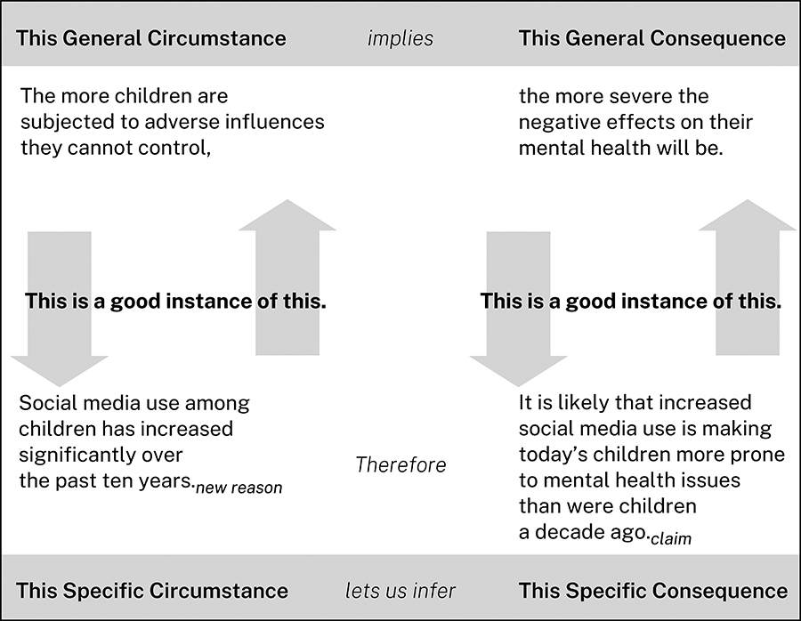

## 8.6 对他人签发的搜查令提出质疑

## 8.6 Challenging Others’ Warrants

最难提出的论证，不仅挑战论点和证据，更挑战研究群体所接受的论证基础。没有比这更难的论证任务了，因为这要求一个群体不仅改变他们的信念，还要改变*他们*的推理*方式*。要成功挑战一个论证基础，你首先必须设想那些接受它的人会如何捍卫它。论证基础可以基于不同类型的支撑论据，因此你必须用不同的方式去挑战它们。

The most difficult arguments to make are those that challenge not just claims and evidence but the warrants a research community embraces. No argumentative task is harder, because in doing so, you ask a community to change not just *what* they believe but *how* they reason. To challenge a warrant successfully, you must first imagine how those who accept it would defend it. Warrants can be based on different kinds of supporting arguments, so you have to challenge them in different ways.

### 8.6.1 基于经验对认股权证提出质疑

### 8.6.1 Challenging Warrants Based on Experience

我们根据自身经验或他人报告做出一些搜查令。

We base some warrants on our experience or on reports by others.

> 如果一个人习惯性说谎，我们就不应该信任他。

> 无风不起浪。

> 当政府债券收益率曲线倒挂时，经济衰退的可能性就很大。

> When people habitually lie, we shouldn’t trust them.

> Where there’s smoke, there’s fire.

> When the yield curve in government bonds inverts, a recession is likely.

要质疑这些证据，你必须质疑经验的可靠性，但这通常并不容易，或者找到不能被当作特殊案例而忽略的反例。

To challenge those warrants, you must challenge the reliability of the experience, which is rarely easy, or find counterexamples that cannot be dismissed as special cases.

### 8.6.2 基于授权对搜查令提出质疑

### 8.6.2 Challenging Warrants Based on Authority

我们之所以相信某些人，是因为他们的专业知识、地位或个人魅力：

We believe some people because of their expertise, position, or charisma:

> 当权威人士X说Y时，Y就一定是Y。

> When authority X says Y, Y must be so.

挑战权威最简单也最友好的方式是指出，在相关问题上，权威人士掌握的证据不足，或者其观点超出了自身专业范围。而最激进的方式则是指出，该权威人士根本就不是权威。

The easiest—and friendliest—way to challenge an authority is to argue that, on the matter in question, the authority does not have all the evidence or reaches beyond its expertise. The most aggressive way is to argue that the source is in fact not an authority at all.

### 8.6.3 对基于知识体系的搜查令提出质疑

### 8.6.3 Challenging Warrants Based on Systems of Knowledge

这些依据都基于一套定义、原则或理论体系：

These warrants are backed by systems of definitions, principles, or theories:

- 数学原理 ：两个奇数相加，结果是一个偶数。
- FROM MATHEMATICS: When we add two odd numbers, we get an even one.
- 生物学知识 ：当一个生物进行有性繁殖时，它的后代与父母双方都不同。
- FROM BIOLOGY: When an organism reproduces sexually, its offspring differ from either parent.
- 法律规定 ：当存在先例时，法官应当遵循先例。
- FROM LAW: When a precedent exists, a judge should follow it.

当你对这些搜查令提出质疑时，“事实”在很大程度上无关紧要。你必须要么挑战制度本身（这总是很困难的），要么证明该案件不符合搜查令的适用范围。

When you challenge these warrants, “facts” are largely irrelevant. You must either challenge the system, always difficult, or show that the case does not fall under the warrant.

### 8.6.4 挑战文化权威

### 8.6.4 Challenging Cultural Warrants

文化依据并非来自个人经验，而是来自整个文化的共同经验，因此似乎是不容置疑的“常识”：

Cultural warrants are backed not by individual experience but by the common experience of an entire culture and therefore seem to be unassailable “common sense”:

> 善有善报恶有恶报。

> 侮辱是正当的，报复是合理的。

> 那些杀不死你的，只会让你更强大。

> What goes around comes around.

> An insult justifies retaliation.

> What doesn’t kill you makes you stronger.

这类搜查令可能会随着时间推移而改变，但变化缓慢。你可以通过提供相互竞争的搜查令或指出其文化特殊性来质疑它们。

Warrants like these may change over time, but slowly. You can challenge them by offering competing warrants or by noting their cultural specificity.

### 8.6.5 质疑方法论依据

### 8.6.5 Challenging Methodological Warrants

这些论据是普遍的思维模式，只有应用于具体案例才有意义。我们用它们来解释抽象推理（许多谚语都源于此）：

These warrants are general patterns of thought with no content until applied to specific cases. We use them to explain abstract reasoning (they are the source of many proverbs):

- 概括：当所有已知的 X 实例都具有品质 Y 时，所有 X 实例可能都具有品质 Y。（*见过一个，就等于见过所有。*）
- GENERALIZATION: When every known case of X has quality Y, then all Xs probably have quality Y. (*Seen one, seen them all.*)
- 类比：如果 X 在大多数方面都像 Y，那么 X 在其他方面也会像 Y。（*有其父必有其子。*）
- ANALOGY: When X is like Y in most respects, then X will be like Y in other respects. (*The acorn doesn’t fall far from the tree.*)
- 征兆：当Y经常出现在X之前、期间或之后时，Y就是X的征兆。（*手冷心暖。*）
- SIGN: When Y regularly occurs before, during, or after X, Y is a sign of X. (*Cold hands, warm heart.*)

哲学家们对这些论证提出了质疑，但在实际论证中，我们只质疑它们的适用性或指出限制条件：*是的，我们可以将 X 类比为 Y，但前提是……*

Philosophers have questioned these warrants, but in matters of practical argumentation, we challenge only their application or point out limiting conditions: *Yes, we can analogize X to Y, but not if . . .*

### 8.6.6 基于信条对搜查令提出质疑

### 8.6.6 Challenging Warrants Based on Articles of Faith

有些权利不容置疑：托马斯·杰斐逊在《独立宣言》中写道：“*我们认为这些真理是不言而喻的，人人生而平等……”。*其他权利包括：

Some warrants are beyond challenge: Thomas Jefferson invoked one when he wrote in the Declaration of Independence, *We hold these truths to be self-evident, that all men are created equal. . . .* Others include

> 如果一项主张是基于自然法，那么它必然是正确的。

> 如果一项主张是基于神圣启示，那么它必然是真的。

> When a claim is based on natural law, it must be true.

> When a claim is based on divine revelation, it must be true.

此类论据并非基于论证，而是基于拥护者的信念，因此几乎不可能用其他论据直接反驳。当论据被用来绕过辩论的来回往复，将某个特定主张置于不容置疑的境地时，我们就脱离了研究和研究论证的范畴。一个被*假定为*真——*而非*基于支持它的理由和证据而被判断为真或至少是合理的主张——不能被视为研究的成果。

Such warrants are backed not by arguments but by the conviction of those who espouse them, and they are therefore almost impossible to contest directly with competing warrants. When a warrant is used to short-circuit the give-and-take of argumentation by placing a particular claim beyond dispute, we have left the domain of research and research argument. A claim *assumed* to be true—rather than *judged* to be true or at least plausible because of the reasons and evidence supporting it—cannot be considered a product of research.

▶ 小贴士：理由、证据和搜查令

▶ Quick Tip: Reasons, Evidence, and Warrants

你可以用两种方式来论证你的理由：提供证据支持，或者从确凿的证据中推导出理由。这两种方式会引出不同类型的论证。研究人员通常更信任第一种方式，所以尽可能地将你的理由建立在可靠的证据之上。比较以下两种论证：

You can justify your reasons in two ways: by offering evidence to support them or by deriving them from a warrant. Each of these ways leads to a different kind of argument. Researchers generally trust the first kind more than the second, so base your reasons on solid evidence when you can. Compare these two arguments:

> 我们应该尽一切努力阻止青少年边开车边发<sub>短信</sub>因为分心驾驶是导致青少年死亡的主要原因之一<sub>。</sub>根据美国疾病控制与预防中心（CDC）的数据，机动车事故造成了12至19岁人群超过三分之一的死亡，而边开车边发短信会成倍增加发生事故的可能性。此外，……<sub>证据</sub>

> 我们应该尽一切努力阻止青少年边开车边发<sub>短信</sub>因为这样做会增加他们发生事故的风险。<sub>理由</sub>一：开车本身就很难，发短信会分散注意力；<sub>理由</sub>二：支持理由一，我们知道，人们在执行复杂任务时如果分心，他们的表现就会受到影响<sub>。理由二与理由一相互关联。</sub>

> We should do what we can to discourage teenagers from texting and driving<sub>claim</sub> because distracted driving is a leading cause of teenage deaths.<sub>reason</sub> According to the CDC, motor vehicle accidents are responsible for over a third of all fatalities among people aged 12–19, and texting while driving exponentially increases the likelihood that any driver will be involved in one. Moreover, . . .<sub>evidence</sub>

> We should do what we can to discourage teenagers from texting and driving<sub>claim</sub> because when they do, their risk of having an accident increases.<sub>reason 1</sub> Driving is difficult and texting a distraction,<sub>reason 2 supporting reason 1</sub> and we know that when people are distracted while performing complex tasks, their performance suffers.<sub>warrant linking reason 2 and reason 1</sub>

如果你和大多数人一样，你可能更倾向于第一种论点。这是因为它的论据并无争议（因此无需赘述），而且它的主张有确凿的证据支持。第二种论点也看似合理，因为理由一和理由二恰好体现了该论据的一般后果和条件。但大多数人仍然希望看到证据。

If you are like most people, you probably preferred the first of these arguments. That’s because its warrant is not controversial (and therefore goes without saying) and its claim is supported by a reason based on solid evidence. That second argument is plausible because reason 1 and reason 2 are good instances of that warrant’s general consequence and condition. But most people still want evidence.

尤其需要指出的是，仅凭证据和理由是无法支持事实主张的（参见6.1 ）：

In particular, you can’t support a claim of fact (see 6.1) with a warrant and reason alone:

> 开车发短信是导致青少年死亡的主要原因之一，<sub>因为</sub>开车发短信会严重分散注意力。<sub>驾驶员</sub><sub>分心</sub>会增加发生严重甚至致命事故的风险。

> Texting and driving is a leading cause of teenage deaths<sub>claim of fact</sub> because texting while driving is very distracting.<sub>reason</sub> When drivers are distracted, they increase their risk of having serious, even fatal accidents.<sub>warrant</sub>

Are you thinking, *I could believe that, but I’d like some proof?* That commonsense response is telling. We can’t just *reason* our way to the conclusion that texting while driving is a *leading* cause of teen fatalities, or even that it causes teen fatalities *at all*. Except in a few fields—some branches of mathematics, philosophy, theology—the way to demonstrate a claim of fact is to show with evidence that what you are claiming is, *in fact*, the case.

教训是：只要有可能，就不要依靠基于理由的复杂推理，而要依靠确凿的证据。

The lesson is this: whenever you can, rely not on elaborate lines of reasoning based on warrants but on hard evidence.

# 9 致谢与回应

# 9 Acknowledgments and Responses

如果论证未能承认其他观点，那么它就是不完整的。本章将阐述如何通过承认并回应他人可能提出的问题、反对意见和替代方案，使你的论证更具说服力。

An argument is not complete if it fails to recognize other points of view. This chapter shows how you can make your argument more convincing by acknowledging and responding to questions, objections, and alternatives others might raise.

再次强调，你的论证核心在于提出一个由证据支撑的理由，并以此为依据展开论断。你可以用其他子理由及其证据来充实论证，或许还可以加入一些将论断与其理由联系起来的论证依据。但是，如果你只向听众提供论断、理由、证据和论证依据——无论这些对你来说多么有说服力——他们仍然可能觉得你的论证单薄，或者轻视他们的观点。论证不仅仅是逻辑构建，它也是一种社会互动。

The core of your argument, again, is a claim supported by reasons based on evidence. You thicken it with additional sub-reasons and their evidence and perhaps also with warrants that connect that claim to its reasons. But if you give your audience only claims, reasons, evidence, and warrants—no matter how compelling these are to you—they may still find your argument thin or dismissive of their views. Arguments are not just logical constructions; they are also social interactions.

要构建一个成功的论证，你不仅需要构建一个由论点、理由和证据构成的坚实体系，还需要将这些论点融入到一场持续的对话中，让听众参与到你的论证中来（参见引言和5.1节）。你可以将你的主要论点呈现为一个听众关心的问题的解决方案（这是引言的重要功能，我们将在第14章）。你还可以预先设想、承认并回应听众可能提出的问题、反对意见和替代方案。在你计划和撰写论文或演示文稿时，听众不会在场提问或提出他们的观点。因此，你必须*设想*他们的问题和观点，并将它们考虑在内。这就是你如何与听众建立合作关系的方式——想象自己正在与他们对话。

To craft a successful argument, you must do more than assemble a sound edifice of claims, reasons, and evidence; you must also bring your audience into your argument by positioning those claims as contributions to an ongoing conversation in which your audience is invested (see the introduction and 5.1). You can do this by presenting your main claim as a solution to a problem your audience cares about (that’s an important function of introductions, which we will talk more about in chapter 14). You can also do it by anticipating, acknowledging, and responding to questions, objections, and alternatives that you think an audience might raise. As you plan and draft your paper or presentation, those others won’t be there to question you or to offer their own views. So you have to *imagine* their questions and views and take them into account. That’s how you establish a cooperative relationship with your audience, by imagining yourself conversing with its members.

本章将向您展示如何设想并应对听众可能就您的论点提出的三种问题：

In this chapter, we show you how to imagine and address three kinds of questions an audience may ask about your argument:

- ▪ 他们可能会质疑研究问题或研究课题，想知道为什么这个论点值得提出。
- ▪ They may challenge the research question or problem it addresses, wondering why the argument is worth making at all.
- 他们可能会质疑你的论点是否合理或连贯——你的主张是否清晰，你的理由和证据是否质量，或者你的逻辑和推理是否合理。
- ▪ They may question your argument’s soundness or coherence—the clarity of your claim, the quality of your reasons and evidence, or your logic and reasoning.
- ▪ 他们可能会要求你考虑其他方案——不同的问题表述方式、其他可能的说法或解决方案、你忽略的证据，或者其他人就你的主题写过什么。
- ▪ They may ask you to consider alternatives—different ways of framing the problem, other possible claims or solutions, evidence you’ve overlooked, or what others have written on your topic.

当你预见、承认并回应所有这三种类型的问题时，你就能构建出一个更容易被听众信任和接受的论点。不要对自己太苛刻：发现论点中的问题时，就是修正它的最佳时机。

When you anticipate, acknowledge, and respond to all three kinds of questions, you create an argument that your audience will more likely trust and accept. Don’t go easy on yourself: the time to fix a problem with your argument is when you find it.

## 9.1 关于您的研究问题的问题

## 9.1 Questions about Your Research Problem

在第一部分中，我们指出，好的研究始于好的问题，这些问题会引出有趣的问题——也就是说，研究界认为重要且值得解决的问题。关于你的研究问题的问题与其说是关于你的论证本身的问题，不如说是论证之前的问题。但如果你无法回答这些问题，你的听众就有可能根本不会关注你的论证。研究者需要能够让听众满意地回答的第一个问题是：*我为什么要关心这个问题？*（参见 I.4.3、2.5 和 6.2。）

In part I, we noted that good research begins with good questions leading to interesting problems—that is, problems research communities believe are significant and worth solving. Questions about your research problem are less questions about your argument itself than questions that precede your argument. But if you can’t answer them, you risk your audience not attending to your argument at all. The first question a researcher needs to be able to answer to an audience’s satisfaction is *Why should I care?* (See I.4.3, 2.5, and 6.2.)

当听众理解研究问题或议题的重要性，并相信你的研究项目——也就是说，当他们相信你的项目能够得出可靠的解决方案或答案——时，他们才会关注你的研究论点。以下是一些可以帮助你建立这种信任的问题。

An audience will care about a research argument when they appreciate the significance of the question or problem it addresses and when they believe in your research project—that is, when they believe your project could lead to a trustworthy solution or answer. Here are some questions you can address to create that confidence.

首先明确你的研究问题：

Start with your research problem:

1. 1.*你认为问题究竟出在哪里？*这个问题带来的成本或后果必须对你和你的听众来说都十分重大。
2. 1. *Why do you think there’s a problem at all?* The costs or consequences of the situation need to be significant, for you and your audience.
3. 2.*你是否正确定义了问题？*确保问题涉及你提出的问题，而不是其他问题，并且问题的范围是可控的（既不太大，也不太小）。
4. 2. *Have you properly defined the problem?* Be sure the problem involves the issue you raise and not another one and that its scope is manageable (not too big, not too small).
5. 3.*问题是实际性的还是概念性的？*也就是说，它的解决方法是采取*行动还是**理解*？
6. 3. *Is the problem practical or conceptual?* That is, does it call for *action* or for *understanding* as its solution?
7. 4.*为什么这个问题很重要？*你需要给出听众能够接受的答案。
8. 4. *Why is the problem significant?* You need an answer to this question that your audience will accept.
9. 5.*你的听众会相信你的项目能够解决问题吗？为什么？*有时，你必须先说服听众，让他们相信你能回答某个研究问题（例如，通过证明你具备必要的能力或专业知识，或者你能获得必要的数据），然后再着手回答这个问题。
10. 5. *Will your audience believe your project will allow you to solve the problem? Why or why not?* Sometimes you have to persuade your audience that you can answer a research question (for instance, by demonstrating that you have the necessary capabilities or expertise or that you can get the necessary data) before you proceed to answer it.

## 9.2 关于你论证合理性的问题

## 9.2 Questions about the Soundness of Your Argument

接下来的问题关乎你论证的核心——你的主张、理由和证据——以及你的论证依据。它们关系到你论证本身的质量，或者说它的各个部分是否衔接得当。首先从你的问题解决方案或主张入手：

These next questions are about the core of your argument—your claim, reasons, and evidence—and your warrants. They concern the quality of your argument itself, or how well its parts hang together. Start with the solution to your problem, or your claim:

1. 1.*你的解决方案或主张是实用的还是概念性的，它是否与问题相符？*
2. 1. *Is your solution or claim practical or conceptual, and does it match the problem?*
3. 2.*你的解决方案或主张是否能解决问题？*
4. 2. *Does your solution or claim solve the problem?*
5. 3.*你的说法是否足够具体，还是过于笼统或模糊？*
6. 3. *Is your claim specific enough, or is it too sweeping or vague?*
7. 4.*你的主张是否可以被质疑？*
8. 4. *Is your claim contestable?*
9. 5.*你的说法是否经过适当的限制，或者你是否提出了过于强硬的说法？*
10. 5. *Is your claim appropriately hedged, or have you stated your claim too strongly?*

注意你的论点中哪些地方看似薄弱，但实际上并非如此。例如，如果你预料到听众会认为你的解决方案存在实际上并不存在的成本，你可以通过承认并回应这种担忧来消除它：

Note where your argument might seem weak but actually isn’t. If, for example, you anticipate that your audience will think your solution has costs that it doesn’t, you can defuse that concern by acknowledging and responding to it:

> 或许有人会认为，关注特定银行的行为会淡化导致金融危机的系统性因素，但事实上，我们的案例研究将表明……

> It might seem that by focusing on the actions of specific banks, we are minimizing the systemic forces that contributed to the financial crisis, but, in fact, our case studies will show . . .

接下来，质疑你的论据——你的理由和证据。首先从你的理由开始：

Next, question your support—your reasons and evidence. Start with your reasons:

1. 1.*你有足够的理由吗？*
2. 1. *Do you have enough reasons?*
3. 2.*你的理由是否一致，还是相互矛盾？*
4. 2. *Are your reasons consistent, or do they contradict each other?*
5. 3.*你的理由与你的主张相关吗？*
6. 3. *Are your reasons relevant to your claim?*

接下来，设想一下你的证据可能会受到哪些质疑。听众可能会质疑证据的类型或时效性：

Next, imagine challenges to your evidence. An audience might question its kind or currency:

1. 1.“你提供的证据类型不适用于我们这个领域”；“我想看到另一种*证据*——确凿的数据，而不是轶事（或者关于真实人物的故事，而不是冷冰冰的数字）。”
2. 1. “You have the wrong kind of evidence for our field”; “I want to see a different *sort* of evidence—hard numbers, not anecdotes (or stories about real people, not cold numbers).”
3. 2.“这个证据已经过时了”；“有比这更新的研究”。
4. 2. “This evidence is out-of-date”; “There’s newer research than this.”

即使你提供的证据类型正确且是最新的，听众仍然可能会质疑其质量：

If you present the right kind of evidence and your evidence is current, an audience might still question its quality:

1. 1.“这不准确。数字对不上。”
2. 1. “It isn’t accurate. The numbers don’t add up.”
3. 2.“这个说法不够精确。‘许多’是什么意思？”
4. 2. “It isn’t precise enough. What do you mean by ‘many’?”
5. 3.“这不够充分，也不具有代表性。你没有获得所有群体的数据。”
6. 3. “It isn’t sufficient or representative. You didn’t get data on all the groups.”
7. 4.“这不具有权威性。史密斯并非这方面的专家。”
8. 4. “It isn’t authoritative. Smith is no expert on this matter.”
9. 5.“这太难懂了。我看不懂你的数据。”
10. 5. “It isn’t understandable. I can’t make sense of your data.”
11. 6. “我不明白。这有什么关系？”
12. 6. “I don’t get it. How is this relevant?”

当听众的利益与你的方案相悖时，他们往往会格外怀疑。因此，如果你觉得自己的证据存在局限性，最好在听众提出异议之前坦诚地承认。总之，在构建论点时，要像你预期中最持怀疑态度的听众那样，检验你的主张、理由和证据。这样，你至少可以回应他们可能提出的最重要的反对意见。在听众进行自我检验之前，让他们看到你已经对你的论点进行了充分的“压力测试”。即便如此，仍然可能有人不为所动。他们要么一开始就不愿被说服（因此一开始就不是真正的对话伙伴），要么就是根本不信服。那就这样吧。

An audience can be particularly skeptical when they have a stake in a solution that differs from yours. So if you feel your evidence has limitations, you may want to admit them candidly, before your audience objects. In sum, when assembling your argument, test your claims, reasons, and evidence as you expect the most skeptical members of your audience will. You can then address at least the most important objections that you can imagine them raising. Show your audience that you’ve put your argument through your own “stress test” before they put it through theirs. Even then, some might remain unpersuaded. Either they were not willing to be persuaded (and therefore not genuine conversational partners to begin with) or they were simply unconvinced. So be it.

## 9.3 设想与你的论点不同的其他方案

## 9.3 Imagining Alternatives to Your Argument

当你意识到自己论点的局限性时，你就能建立起可信度，因为这向听众表明你提出的论点是真诚的，并且你公平地对待他们。如果你不仅展现出你理解自己论点的优势和局限性，而且还展现出你理解并思考过其他替代方案，那么你的可信度会更高。

When you recognize your argument’s limitations, you build credibility by showing your audience that you are making an honest case and dealing with them fairly. You will seem even more credible if you show not just that you understand the strengths and limitations of your argument, but also that you understand and have thought about the alternatives to it.

那些与你世界观不同的人，不仅可能持有与你不同的观点，而且可能对术语的定义不同，推理方式不同，甚至提供的证据也不同。不要简单地忽视这些差异；相反，要承认并回应其中最重要的差异，将它们融入你的论证中。

Those who see the world differently from you are likely not just to hold views that differ from yours but also to define terms differently, to reason differently, even to offer different evidence. Do not simply dismiss these differences; instead, bring the most important of them into your argument by acknowledging and responding to them.

如果你对研究主题和目标受众非常了解，你可以尝试自己设想其他可能性。但通常来说，找到其他观点的最佳方法是查阅资料。在第四章中，我们鼓励你在研究过程中积极利用*资料，不仅将其作为信息来源，更要激发自己的思考。资料中也提供了现成的其他观点，你可以对它们做出回应。*

If you know your subject and audience very well, you can try to imagine those alternatives yourself. But usually the best way to identify alternative views is to look to your sources. In chapter 4, we encouraged you to actively *engage* your sources during your research, to use them not just as sources of information but to stimulate your own thinking. Your sources also offer a ready supply of alternative views that you can respond to.

你可以把二手资料看作是围绕你的主题、问题或难题展开的讨论的书面记录。了解这些讨论能让你参与其中。阅读资料时，注意它们提出的观点与你不同的地方，它们采用的方法不同的地方，它们关注问题的不同方面的地方等等。尤其要注意你和资料在哪些地方存在分歧，以及分歧的原因。还要注意不同资料之间是否存在分歧。所有这些分歧都能帮助你找到其他可以纳入自己论证的选项。如果你知道你会如何回应某个资料，就在阅读时把这种回应添加到你的笔记中。

You can think of your secondary sources as a written record of the conversation about your topic, question, or problem. Knowing that conversation allows you to contribute to it. When you read your sources, note where they advance claims different from yours, take different approaches, focus on different aspects of the problem, and so on. Note especially where—and why—you and your sources disagree. Also note where one source disagrees with another. All those disagreements can help you identify alternatives to acknowledge in your own argument. If you know how you would respond to a particular source, add that response to your notes as you read.

你不仅可以回应信息来源的主张，还可以回应他们的理由、证据和推理过程。如果你发现某个信息来源，你的受众可能会认真对待，但你却觉得它缺乏说服力，不要忽略它。相反，要解释原因。最后，信息来源还能帮助你设想受众，并预测他们对你的论点的反应。通常，你的受众会与信息来源的作者群体相似——有时甚至可能包括他们自己。

You can respond not only to your sources’ claims but also to their reasons and evidence, and their reasoning. If you find a source that your audience might take seriously but that you don’t find persuasive, don’t ignore it. Instead, explain why. Finally, your sources also help you imagine your audience and anticipate their reactions to your argument. Often your audience will be made up of people like your sources’ authors—and sometimes may even include them.

## 9.4 决定承认什么

## 9.4 Deciding What to Acknowledge

如果你能设想出几种可能的替代方案和反对意见，你就会面临一个“金发姑娘”时刻：承认太多，会分散听众对论点核心的注意力；承认太少，又会显得你轻视甚至无视听众的观点。你需要找到一个“恰到好处”的承认数量。

If you can imagine just a few alternatives and objections to your argument, you’ll face a Goldilocks moment: Acknowledge too many and you distract from the core of your argument; acknowledge too few and you seem dismissive or even ignorant of your audience’s views. You need to figure out how many acknowledgments will feel “just right.”

### 9.4.1 选择回应的内容

### 9.4.1 Choosing What to Respond To

为了缩小备选方案和反对意见的范围，请考虑以下优先事项：

To narrow your list of alternatives and objections, consider these priorities:

- ▪ 你可以反驳的、看似合理的弱点指控
- ▪ plausible charges of weaknesses that you can rebut
- ▪ 您所在领域中重要的其他论证思路
- ▪ alternative lines of argument important in your field
- ▪ 观众*希望*看到的替代结论
- ▪ alternative conclusions that an audience *wants* to be true
- ▪ 观众知晓的替代证据
- ▪ alternative evidence that an audience knows
- ▪ 你必须回应的重要反例
- ▪ important counterexamples that you have to address

寻找机会重申你的论点。例如，如果听众可能误解了你的论点范围，请承认他们的疑虑，并通过澄清来提醒他们你的观点：

Look for opportunities to reiterate parts of your argument. For example, if an audience might misconstrue your argument’s scope, acknowledge their concern and use your clarification to remind them of your point:

> 养殖鱼类中重金属污染确实令人担忧，但我们的研究重点是野生捕捞鱼类的营养价值……

> There is reason to worry about heavy metal contamination in some farmed fish, but our study focuses on the nutritional value of wild-caught . . .

或者，如果你的听众可能想到与你的方案相近的替代方案，那就利用这一点来强调你的方案的优点：

Or if your audience might think of an alternative solution close to yours, use it to emphasize the virtues of your solution:

> 大多数研究者认为，规则和其他形式的正式写作指导非但不能提高写作水平，反而会降低写作效率，因为写作“是一种无意识的意义建构行为，而非有意识地遵循规则的过程”。这在写作过程的某些方面是正确的：作者在撰写句子时不应该参考规则。但写作不仅涉及起草，还包含许多有意识的过程。本文将展示哪些正式指导对写作的*有意识*层面有效，哪些无效……

> Most researchers argue that rules and other forms of formal writing advice degrade rather than improve performance because writing “is a non-conscious act of making meaning, not a conscious process of following rules.” That is true for parts of the process: writers should not consult rules as they draft sentences. But writing involves not just drafting but many conscious processes as well. What we show here is what kinds of formal advice do and do not work for *conscious* aspects of writing. . . .

最后，要承认一些可能特别吸引观众的选择，但前提是你能做出实质性的回应，而不是轻视它们。

Finally, acknowledge alternatives that may particularly appeal to your audience but only if you can respond substantively, without appearing to brush them aside.

### 9.4.2 承认论点中的不足

### 9.4.2 Acknowledging Weaknesses in Your Argument

如果你发现论证中存在无法弥补的漏洞，可以尝试重新定义问题或重构论证以规避它。但如果实在无法做到，你将面临一个艰难的抉择。你可以选择忽略这个漏洞，希望听众不会注意到。但这并不诚实。如果他们注意到了，就会质疑你的能力；如果他们认为你试图掩盖漏洞，就会质疑你的诚实。我们的建议或许听起来有些天真，但却行之有效。坦诚地承认问题，并做出回应。

If you discover a weakness in your argument that you cannot fix, try to redefine your problem or rebuild your argument to avoid it. But if you cannot, you face a tough decision. You could just ignore the weakness and hope your audience doesn’t notice it. But that’s dishonest. If they do notice it, they will doubt your competence, and if they think you tried to hide it, they will question your honesty. Our advice may seem naive, but it works. Candidly acknowledge the issue and respond that

- ▪ 你的论点其余部分足以弥补这一不足。
- ▪ the rest of your argument more than compensates for the weakness.
- ▪ 虽然这个弱点很严重，但更多的研究将会找到克服它的方法。
- ▪ while the weakness is serious, more research will show a way around it.
- ▪ 虽然这个缺陷使得我们无法完全接受你的说法，但你的论证为这个问题提供了重要的见解，并指出了一个更好的答案应该具备哪些特征。
- ▪ while the weakness makes it impossible to accept your claim fully, your argument offers important insight into the question and suggests what attributes a better answer would have.

有时，研究人员会化失败为成功，他们将自己想要支持但未能支持的论点视为一个其他人可能认为合理的假设。然后，他们会证明这个假设是不合理的：

Occasionally researchers turn failure into success by treating a claim they wanted to support but couldn’t as a hypothesis that others might find reasonable. Then they show why it isn’t:

> 人们或许会认为，当陪审员听到的案件事实侧重于受害者的痛苦时，他们更有可能指责被告。毕竟，这是原告律师的惯用伎俩，也是我们预期研究结果会证实的。但事实上，我们发现两者之间并无关联……

> It might seem that when jurors hear the facts of a case in a form that focuses on victims’ suffering, they will be more likely to blame the accused. That is, after all, the standard practice of plaintiffs’ lawyers and what we expected our research to affirm. But in fact, we found no correlation between . . .

### 9.4.3 承认你无法回答的问题

### 9.4.3 Acknowledging Questions You Can’t Answer

初学者有时试图在某个主题上占据绝对主导地位，提出一个不容置疑、唯有完全赞同的论点。这是个误区。经验丰富的研究人员明白，研究的目标通常是增进研究群体的集体理解，推动对话持续进行。事实上，最具启发性的研究往往不是回答现有问题，而是提出我们尚未想到的新问题。对于解决概念性问题的研究而言，这一点尤为重要，但对于应用研究也同样适用。

Beginning researchers sometimes aim to have the last word on a topic, to make an argument that allows for no response but total agreement. That’s a mistake. Experienced researchers know that the goal of research is usually to advance the collective understanding of a research community, to keep its conversation going. In fact, the most stimulating research is often that which provides not answers to existing questions but new questions we haven’t yet thought to ask. This is especially true for research addressing conceptual problems, but it can be true for applied research as well.

与其假装自己掌握了所有答案，不如坦诚地面对仍然存在的问题，这样有见识的听众会更认可你的论点，也会更尊重你这个人。

A knowledgeable audience will think better of your argument and of you if, rather than pretending you have all the answers, you are candid about questions that still remain.

## 9.5 将你的回应构建成子论点

## 9.5 Framing Your Responses as Sub-arguments

你不能仅仅通过提出相互矛盾的观点来回应其他方案和反对意见。即使是最基本的回应也需要解释：

You can’t respond to alternatives and objections simply by asserting competing claims. Even a minimal response demands explanation:

> 虽然一些机构，例如美国预防服务工作组（USPSTF），不建议对55岁以上的男性进行常规PSA筛查，但<sub>我们</sub>特别关注筛查对高危人群（例如有前列腺癌家族史的男性）的价值。<sub>解释为何这种反对意见不适用。</sub>

> While some organizations, such as the US Preventive Services Task Force (USPSTF), recommend against routine PSA screening of men over 55,<sub>acknowledgment of objection</sub> we are concerned specifically with the value of screenings for higher-risk populations such as men with a family history of prostate cancer.<sub>explanation of why objection does not apply</sub>

初步解释或许就足够了，但如果你觉得还需要更多帮助，请提供额外支持：

That initial explanation may be enough, but if you feel you need more, offer additional support:

> 尽管一些组织，例如美国预防服务工作组（USPSTF），不建议对55岁以上的男性进行常规PSA筛查，但<sub>我们</sub>特别关注对高危人群（例如有前列腺癌家族史的男性）进行筛查的<sub>价值</sub>我们承认，常规PSA筛查会导致过度诊断和过度治疗，使许多男性不必要地承受不良副作用<sub>。但Tsai等人（2021）的研究表明，</sub><sub>结合</sub>有效的咨询，对高危人群进行检测可以降低……的发生率。

> While some organizations, such as the US Preventive Services Task Force (USPSTF), recommend against routine PSA screening of men over 55,<sub>acknowledgment of objection</sub> we are concerned specifically with the value of screenings for at-risk populations such as men with a family history of prostate cancer.<sub>explanation why objection does not apply</sub> We recognize that routine PSA screenings have resulted in overdiagnosis and overtreatment, subjecting many men to adverse side effects unnecessarily,<sub>additional concession to the objection</sub> but Tsai et al. (2021) have shown that coupled with effective counseling, the testing of at-risk populations reduces the incidence of . . .<sub>report of additional evidence</sub>

如果你觉得还需要更多论据，就需要提出完整的子论点。同样，在回应各种选择时，你面临着一个“恰到好处”的选择：既不能太多，也不能太少。只有经验才能教会你如何找到这种平衡。所以，观察专家是如何做到这一点的，并效仿他们。

If you feel you need more still, you will need to offer a full sub-argument. Again, when responding to alternatives, you face a Goldilocks choice: not too much, not too little. Only experience can teach you how to find this balance. So notice how experts achieve it and do likewise.

## 9.6 致谢与回应的词汇

## 9.6 The Vocabulary of Acknowledgment and Response

当你想回应反对意见或替代方案时，你需要决定给予它多少关注：从仅仅提及反对意见并予以驳回，到详细阐述，不一而足。我们的建议大致按此顺序呈现，从最简短的开始。从最轻蔑的态度到最持久和尊重的态度。（方括号和斜杠表示其他选项。）

When you want to acknowledge and respond to an objection or alternative, you have to decide how much attention to give it: options range from just mentioning an objection and dismissing it to addressing it at length. We present our advice roughly in that order, from the briefest and most dismissive to the most sustained and respectful. (Brackets and slashes indicate alternative choices.)

### 9.6.1 承认反对意见和替代方案

### 9.6.1 Acknowledging Objections and Alternatives

用能够体现你对反对意见或替代方案重视程度的语言来回应。以下是一些建议。

Acknowledge an objection or alternative in language that shows how much weight you give it. Here are some options.

1. *1. 你可以用“尽管如此”、**“不管怎样*”或*“尽管如此”*来淡化反对意见或替代方案：
   > 1. 尽管**市长**声称她想降低房产税，<sub>但</sub>对她最新预算提案的<sub>回应</sub>
   > 2. *though、**while*和*even* though 的用法相同：
   > 3. 尽管一些中小型银行倒闭，但**零售**银行业<sub>整体依然保持强劲势头……</sub><sub>回应</sub>
   > 4. 2. 你可以用*seem*、*appear、**may*或*could*等词语，或者用 plausibly、 justifiably *、* reasonablely 、*surprisingly**甚至*certain 等*副词*来间接表示认可：
   > 5. 在甘地的个人日记中，他表现出一些看似**临床**抑郁症的症状<sub>。</sub>但那些观察过他的人……<sub>回应</sub>
   > 6. 这项提议**或许有**一定价值，<sub>我们承认这一点，但我们</sub>……<sub>回应</sub>
   > 7. 3. 你可以将反对意见或替代方案归因于未具名的来源，这会增加一些可信度：
   > 8. 人们很容易认为税收应该……（承认这<sub>一点</sub>**）**<sub>。</sub>但还有另一种**解释****/论证思路/解释/可能性。**
   > 9. 一些证据（**可能/或许/可以/可以/确实**）表明我们应该……，承认**这一点，**<sub>但是</sub>……<sub>回应</sub>
   > 10. 4. 你可以将反对意见或替代方案归因于一般的对话者，从而赋予其更大的分量：
   > 11. 有些**人**可能**会**说**/认为/争论/声称/指责/反对**碳捕获技术并非……<sub>承认</sub>但事实上……<sub>回应</sub>
   > 12. 尽管[**一些研究人员/评论家/学者]**<sub>认为</sub>……，但我们的研究表明……
   > 13. 请注意，如果您过早或过度贬低您不同意的观点，或者尤其是持有这些观点的人，您可能会削弱您的信誉和论点。
   > 14. 这种**不切实际的说法**是……
   > 15. 一些**天真的**研究人员声称……
   > 16. 这位**经常粗心大意的**历史学家甚至声称……
   > 17. 批评应该留到回应时再说，而且要针对作品本身，而不是针对个人。
   > 18. 5. 你可以用自己的声音承认反对意见或替代方案，使用*“我”*或*“我们”*，被动语态动词，或者使用诸如*“诚然”、* *“肯定”* 、*“当然”*等词语或短语，以此承认其某种合理性：
   > 19. 我**理解/知道/意识到，**进步人士相信……<sub>承认但……</sub><sub>回应</sub>
   > 20. 热泵比天然气炉更高效，这是**事实**。然而<sub>……</sub>
   > 21. 必须承认**，没有确凿****的**<sub>证据</sub>证明……然而，……
   > 22. [**诚然/当然/承认/属实/毋庸置疑/当然**]，亚当斯声称……<sub>承认</sub>然而……<sub>回应</sub>
   > 23. 我们[**会/可以/可能/也许**][**说/认为/声称/认为**]诸如免费心理健康筛查之类的项目可能会阻碍 ……<sub>承认这一点，但</sub>这些影响被……<sub>回应所抵消。</sub>
2. 1. You can downplay an objection or alternative by introducing it with *despite*, *regardless of*, or *notwithstanding*:
   > 1. [**Despite/Regardless of/Notwithstanding**] the mayor’s claims that she wants to reduce property taxes,<sub>acknowledgment</sub> her latest budget proposals suggest that . . .<sub>response</sub>
   > 2. Use *although*, *while*, and *even though* in the same way:
   > 3. [**Although/While/Even though**] Even though some smaller and midsize banks have failed,<sub>acknowledgment</sub> the retail banking sector as a whole remains strong . . .<sub>response</sub>
   > 4. 2. You can signal an acknowledgment indirectly with *seem*, *appear*, *may*, or *could*, or with an adverb like *plausibly*, *justifiably*, *reasonably*, *surprisingly*, or even *certainly*:
   > 5. In his personal journals, Gandhi expresses what [**seem/appear**] to be symptoms of clinical depression.<sub>acknowledgment</sub> But those who observed him . . .<sub>response</sub>
   > 6. This proposal [**may have/plausibly has**] some merit,<sub>acknowledgment</sub> but we . . .<sub>response</sub>
   > 7. 3. You can attribute an objection or alternative to an unnamed source, which gives it a little weight:
   > 8. It is easy to [**think/imagine/say/claim/argue**] that taxes should . . .<sub>acknowledgment</sub> But there is [**another/alternative/possible**] [**explanation/line of argument/account/possibility**].<sub>response</sub>
   > 9. Some evidence [**might/may/can/could/does**] [**suggest/indicate/point to/lead some to think**] that we should . . . ,<sub>acknowledgment</sub> but . . .<sub>response</sub>
   > 10. 4. You can attribute an objection or alternative to a generic interlocutor, giving it more weight:
   > 11. There are [**some/many/a few**] who [**might/may/could/would**] [**say/think/argue/claim/charge/object**] that carbon capture technologies are not . . .<sub>acknowledgment</sub> But, in fact, . . .<sub>response</sub>
   > 12. Although [**some researchers/critics/scholars**] have argued that . . . ,<sub>acknowledgment</sub> our research shows . . .
   > 13. Note that you can weaken your ethos and your case if you prematurely or excessively denigrate views you disagree with or, especially, those who hold them.
   > 14. The **ill-conceived claim** that . . .
   > 15. Some **naive** researchers have claimed that . . .
   > 16. The **often-careless** historian has even claimed that . . .
   > 17. Save criticism for the response, and direct it at the work rather than the person.
   > 18. 5. You can acknowledge an objection or alternative in your own voice, using *I* or *we*, a passive verb, or a word or phrase such as *admittedly*, *granted*, *to be sure*, and so on, which concedes it some validity:
   > 19. I [**understand/know/realize**] that progressives believe . . . ,<sub>acknowledgment</sub> but . . .<sub>response</sub>
   > 20. It is [**true/possible/likely**] that heat pumps are more efficient than natural-gas furnaces.<sub>acknowledgment</sub> However, . . .<sub>response</sub>
   > 21. It [**must/should/can**] be [**admitted/acknowledged/noted/conceded**] that no good evidence proves that . . .<sub>acknowledgment</sub> Nevertheless, . . .
   > 22. [**Granted/Certainly/Admittedly/True/To be sure/Of course**], Adams has claimed . . .<sub>acknowledgment</sub> However, . . .<sub>response</sub>
   > 23. We [**would/could/can/might/may**] [**say/argue/claim/think**] that programs such as free mental health screenings might discourage . . . ,<sub>acknowledgment</sub> but these effects are outweighed by . . .<sub>response</sub>

### 9.6.2 回应反对意见和替代方案

### 9.6.2 Responding to Objections and Alternatives

你的回应可以以表示不同意见的词语或短语开头，例如*“但是”*、*“然而”*或*“另一方面”。*如果你还没有解释你回应的依据，你可能需要用自身的理由，甚至一个完整的从属论证来支持它。

Begin your response with a term or phrase that signals disagreement, such as *but*, *however*, or *on the other hand*. If you haven’t already explained the basis of your response, you may have to support it with its own reason or even with a complete subordinate argument.

你可以用各种方式回应，从委婉到直率不等。

You can respond in ways that range from tactful to blunt.

1. 1. 你可能会后悔的不是信息来源不明，而是*自己*没有完全理解：
   > 1. 但是[**我不太明白/我很难理解/我不明白**] X 是如何声称，当……<sub>回应</sub>
   > 2. 2. 或者你可以指出，存在一些尚未解决的问题：
   > 3. 但这里还有**其他问题** ……/但仍然存在 ……<sub>响应的</sub>**问题**
   > 4. 3. 你可以采取更强硬的回应，声称对方承认的立场无关紧要或不可靠：
   > 5. 但即便这种观点很有见地，<sub>承认这一点也[忽略/与</sub><sub>当前</sub>问题无关**/不相干] 。**
   > 6. 但[**证据/推理]** [**不可靠/站不住脚/薄弱]** <sub>。</sub>
   > 7. 但这种论点[**站不住脚/站不住脚/混乱/过于简单**<sub>]</sub>。
   > 8. <sub>但</sub>这种论点**忽略了**关键因素。
   > 9. 你必须决定回应的措辞应该有多直白。如果某个替代方案显然是错误的，那就直接指出来，但再次强调，重点要放在工作本身，而不是人身上。
   > 10. 4. 当你认为其他研究人员似乎没有认真考虑某个问题时，通常应该礼貌地指出来。以下是一些例子：
   > 11. 史密斯的证据固然重要，<sub>我们承认这一点，但我们</sub> <sub>必须</sub>**审视所有可用的证据。**
   > 12. 这解释了部分问题，<sub>也承认了这一点，但问题</sub> **过于复杂，无法用单一的解释来**<sub>概括</sub>
   > 13. 这一原则在很多情况下都成立，<sub>但</sub> **并非所有**<sub>情况都如此</sub>。
2. 1. You can regret not that the source is unclear, but that *you* don’t entirely understand:
   > 1. But [**I do not quite understand how/I find it difficult to see how/It is not clear to me how**] X can claim that, when . . .<sub>response</sub>
   > 2. 2. Or you can note that there are unsettled issues:
   > 3. But there are **other issues here** . . . /But there **remains the problem of** . . .<sub>response</sub>
   > 4. 3. You can respond more forcefully, claiming the acknowledged position is irrelevant or unreliable:
   > 5. But as insightful as that may be,<sub>acknowledgment</sub> it [**ignores/is irrelevant to/does not bear on**] the issue at hand.<sub>response</sub>
   > 6. But the [**evidence/reasoning**] is [**unreliable/shaky/thin**].<sub>response</sub>
   > 7. But the argument is [**untenable/weak/confused/simplistic**].<sub>response</sub>
   > 8. But the argument [**overlooks/ignores/misses**] key factors.<sub>response</sub>
   > 9. You have to decide how blunt your response should be. If an alternative seems obviously wrong, say so, but again focus on the work rather than the person.
   > 10. 4. When you think another researcher seems to have not thought through an issue carefully, you usually should say so civilly. Here are a few possibilities:
   > 11. Smith’s evidence is important,<sub>acknowledgment</sub> **but we must look at all the available evidence**.<sub>response</sub>
   > 12. That explains some of the problem,<sub>acknowledgment</sub> **but it is too complex for a single explanation**.<sub>response</sub>
   > 13. That principle holds in many cases,<sub>acknowledgment</sub> **but not in all**.<sub>response</sub>

▶ 小贴士：三种可预见的争论

▶ Quick Tip: Three Predictable Disagreements

你的听众中至少有一部分人可能会想到以下三种替代方案。

There are three kinds of alternatives that at least some members of your audience are likely to think of.

1. 1.**除了你声称的原因之外，还有其他原因。**如果你的论点是关于因果关系，请记住，任何结果都不可能只有一个原因，反之亦然。如果你认为 X 导致 Y，每个人都会想到其他原因。蜜蜂种群的崩溃可能是由于杀虫剂的使用，但了解蜜蜂的人还可以列出其他可能的因素，包括栖息地丧失、疾病、转基因作物和寄生虫。因此，如果你只关注众多原因中的一个，也要承认其他原因的存在。如果你觉得听众可能认为某些原因比你给予的更多关注，也要承认这种观点，并解释你为什么弱化了它。
2. 1. **There are causes in addition to the one you claim.** If your argument is about cause and effect, remember that no effect has a single cause and no cause has a single effect. If you argue that X causes Y, everyone will think of other causes. Honeybee colonies may be collapsing because of pesticide use, but someone knowledgeable about honeybees could also list other possible factors, including loss of habitat, disease, genetically modified crops, and parasites. So if you focus on one cause out of many, acknowledge the others. And if you feel your audience might think that some cause deserves more attention than you give it, acknowledge that view and explain why you de-emphasized it.
3. 2.**那么这些反例呢？**无论你的证据多么充分，一些持怀疑态度的听众很可能会想到一些例外情况和反例，他们认为这些反例会削弱你的论点。因此，你必须首先考虑这些反例，承认那些比较合理的反例，尤其是一些生动的例子，然后解释为什么你认为它们不像那些怀疑论者认为的那样具有破坏性。当你对气候变化等变化范围很大的现象提出论断时，尤其要谨慎。不了解统计推理的人会关注异常情况，即使它符合正态分布：迈阿密寒冷的七月四日并不能反驳气候变化的说法，正如蒙特利尔温暖的元旦也不能证明气候变化的说法一样。
4. 2. **What about these counterexamples?** No matter how rich your evidence, some skeptical members of your audience are likely to think of exceptions and counterexamples that they believe undermine your argument. So you must think of them first, acknowledge the more plausible ones, especially if they are vivid, and then explain why you don’t consider them as damaging as those skeptics might. Be particularly wary when you make claims about a phenomenon with a wide range of variation, such as the climate. People who do not understand statistical reasoning will focus on an aberrant case, even though it falls within a normal distribution: a cold Fourth of July in Miami does not disprove a claim about climate change, any more than a warm New Year’s Day in Montreal proves it.
5. 3.**我对 X 的定义与你不同。对我来说，X 的意思是……**如果读者接受你的定义，他们就更容易接受你的论点：如果你正在研究社交媒体“成瘾”，你的读者必须理解你使用这个词的含义。你是字面意义上的（即社交媒体会像香烟和某些毒品一样引发生理上的渴望），还是比喻意义上的（仅仅是指难以戒除）？你可以找到各种各样的定义，从字典里的几行字到医学参考书里的几页篇幅。但无论这些资料怎么说，人们人们往往会重新定义遇到的术语，以符合自己的观点。大型科技公司的高管辩称，社交媒体不会让人上瘾，因为人们可以随时停止使用；而批评者则认为，社交媒体之所以会让人上瘾，是因为很多人无法停止使用。

   当你的论证依赖于某个术语的含义时，请先定义该术语以支持你的论点，并为你的定义提供辅助论据。不要将字典定义视为权威（切勿以“根据*韦氏词典，* ‘成瘾’的意思是……”开头）。注意可能存在的、合理的替代定义，并加以说明。如果你使用了一个既有专业术语又有常用含义的术语（例如*社会*阶层或理论*），*请说明该常用含义，并解释你为何采用专业术语的含义。反之，如果你没有按照专家预期的方式使用某个专业术语，也请说明这一点，并解释你为何选择其他含义。
6. 3. **I don’t define X as you do. To me, X means . . .** It helps an audience accept your claim if they accept your definitions: if you are researching “addiction” to social media, your audience must understand what you mean by that term. Do you mean it literally (that is, that social media creates physical cravings like cigarettes and some drugs) or just metaphorically (that it’s merely hard to stop using)? You can find definitions ranging from a few lines in a dictionary to pages in a medical reference work. But regardless of what those sources say, people tend to redefine terms they encounter to suit their own views. Big-tech executives have argued that social media is not addictive because people are free to stop using it; their critics argue that it is addictive because many people can’t.

   When your argument hinges on the meaning of a term, define it to support your solution and offer a subordinate argument for your definition. Don’t treat a dictionary definition as authoritative (never begin, “According to *Webster’s*, ‘addiction’ means . . .”). Be aware of plausible alternative definitions that you may need to acknowledge. If you use a technical term that also has a common meaning (like *social class* or *theory*), acknowledge that common meaning and explain why you have adopted the technical one. Conversely, if you do not use a technical term as an expert would expect you to, acknowledge that and explain why you’ve opted for another meaning.

# 第四部分

# Part IV

# 陈述你的论点

# Delivering Your Argument

# 序幕

# Prologue

# 计划、写作和思考

# Planning, Writing, and Thinking

并非所有研究项目最终都会以正式论文或报告的形式呈现。但如果你的项目最终会以论文或报告的形式呈现，那么你最终需要一个计划。许多作者一开始并没有计划，但随着思路逐渐清晰，他们不得不舍弃一些虽好但无关紧要的页面。另一些人则离不开详尽的提纲、摘要或故事板。还有一些人会在动笔之前，先在脑海中构思出草稿。你需要找到自己开始撰写初稿的方法，但如果你从一开始就通过摘要、分析和评论等方式不断写作，逐步完善论文，就能为最终的写作做好准备。

Not all research projects culminate in a formal paper or presentation. But if yours will, you will eventually need a plan. Many writers begin without a plan, but as things become clearer, they have to discard good but irrelevant pages. Others can’t get going without elaborate outlines, summaries, or storyboards. And some of us compose drafts in our heads well before turning to a serious draft in writing. You have to find your own way to start a first draft, but you can prepare for that moment if you keep writing your way toward the paper from the start through summaries, analyses, and critiques.

以下是判断你是否准备好制定草案的标准：

Here’s how you know when you’re ready to plan a draft:

- ▪ 你知道你的受众是谁，他们了解什么，以及他们为什么应该关心你的问题。
- ▪ You know who your audience is, what they know, and why they should care about your problem.
- ▪ 你知道你想展现什么样的精神或性格。
- ▪ You know the kind of ethos or character you want to project.
- 你可以用两三句话概括你的问题和答案。
- ▪ You can sketch your question and its answer in two or three sentences.
- ▪ 您可以概述支持您主张的理由和证据。
- ▪ You can sketch the reasons and evidence supporting your claim.
- ▪ 你知道你的听众可能不认为某个理由与某个主张相关，并且可以陈述将两者联系起来的论据。
- ▪ You know when your audience may not see the relevance of a reason to a claim and can state the warrant that connects them.
- ▪ 你知道可能会被提出的问题、替代方案和反对意见，并且你可以回应它们。
- ▪ You know the questions, alternatives, and objections that are likely to be raised, and you can respond to them.

即使有了计划并准备开始写作，经验丰富的作家也知道，他们不会一蹴而就地完成一部作品。他们知道自己会走一些弯路，但也会有一些新的发现，甚至可能需要重新思考整个项目。他们也知道，早期草稿中的很多内容最终都不会出现在最终稿中，所以他们会尽早开始，以便留出修改的时间。

Even when they have a plan and are ready to draft, though, experienced writers know that they won’t march straight through to a finished product. They know they’ll make some wrong turns but also some new discoveries and maybe even rethink their whole project. They also know that a lot of their early drafting will not make it into their final draft, and so they start early enough to leave time for revision.

第四部分将指导您完成最终论文或演示文稿的撰写过程。第十章我们将探讨规划和草拟，第十一章将讲解如何组织论证。第十二章我们将讨论引用和整合资料来源这项颇具挑战性的任务。第十三章我们将探讨如何以可视化的形式呈现定量数据，第十四章将讲解如何撰写有效的引言和结论。第十五章我们将介绍如何以清晰简洁的风格进行写作。最后，第十六章我们将讨论如何以演示文稿的形式呈现您的研究成果。

Part IV will lead you through the process of creating your final paper or presentation. In chapter 10, we walk through planning and drafting, then in chapter 11 organizing your argument. In chapter 12, we discuss the demanding task of incorporating and citing sources. In chapter 13, we discuss how to present quantitative data in visual form, and in chapter 14 how to write effective introductions and conclusions. In chapter 15, we offer principles for writing in a clear and direct style. Finally, in chapter 16, we discuss how to deliver your research as a presentation.

在此之前，让我们先来探讨一项至关重要的研究活动：与他人分享。正如本书反复强调的，与感兴趣的研究群体分享研究成果是研究的最终目标。正因如此，我们才会提出好的问题，搜寻可靠的数据，并构建和论证一个合理的答案。有时，我们研究成果的读者可能只有一位老师，至少在最初阶段是这样。你或许会想：“*我的老师对我的研究课题了如指掌。除了证明自己能做到之外，我写研究报告还能获得什么呢？”*其实，老师的职责不仅仅是验证你是否具备研究和写作能力，更重要的是帮助你培养这些技能。此外，我们写作不仅是为了分享研究成果，也是为了在分享之前不断完善它。

Before that, let’s consider an essential activity of research: sharing it with others. As we stress throughout this book, sharing the results of our research with an interested research community is the ultimate goal of research. It is why we find a good question, search for sound data, and formulate and support a good answer. Sometimes, the audience for our work may be a single teacher, at least initially. You may think, *My teacher knows all about my topic. What do I gain from writing up my research, other than proving I can do it?* Well, your teacher’s job is not just to verify that you can research and write but to help you develop these skills. Another answer is that we write not only to share our work, but to improve it before we do.

*除了分享我们的研究成果之外，我们在研究过程中*进行写作至少还有三个原因：

Beyond sharing our research, there are at least three reasons to write *as* we research:

- ▪ 写下来以便记住：
  > 1. 经验丰富的研究人员首先会做笔记来记住他们读过的内容。少数天赋异禀的人能够记住大量信息，但我们大多数人都需要记笔记。否则，你很可能会忘记，或者更糟的是，记错。
  > 2. ▪ 写作是为了理解：
  > 3. 写作的第二个原因是发现我们阅读的内容和收集的数据中更大的规律。当你以新的方式整理和重新整理研究结果时，你会发现新的意义。各种关联和复杂情况。即使你能记住所有信息，你也需要帮助才能理清方向各异的论点，梳理错综复杂的关系，并解决专家之间的分歧。

  术语梳理：答案、解决方案、主张、观点

  在第一部分和第二部分中，我们使用*“答案”*和*“解决方案”来*指代解决您研究核心问题的命题。在第三部分中，我们使用“*主张”*来指代您论证的答案或解决方案，并使用“主要*主张”来指代*构成您其余论证所支持的关键断言。在第四部分中，我们使用*“论点”*来指代论文中陈述主张的句子（有些人使用*“论题”*）。答案*、**解决方案*、主张和论点*——所有*这些术语都指代同一事物，只是表达方式不同。
  > 1. 这就是为什么经验丰富的研究人员不会等到收集到所有需要的数据后才开始写作：他们从项目开始之初就开始写作，以帮助他们以新的方式整理信息。
  > 2. ▪ 写作以检验你的思考：
  > 3. 写作的第三个原因是将你的想法从脑海中转移到纸上，这样你才能*真正*看清自己的想法。几乎我们所有人，无论是学生还是职场人士，都认为自己的想法比写出来之后更有说服力。只有将想法从纷乱的思绪中剥离出来，并以条理清晰的形式呈现出来，你才能真正了解自己的想法有多好，而这种形式也便于你和读者进行研究。
- ▪ Write to remember:
  > 1. Experienced researchers first write to remember what they have read. A few talented people can hold in mind masses of information, but most of us need to take notes on what we read. If you don’t, you are likely to forget or, worse, misremember.
  > 2. ▪ Write to understand:
  > 3. A second reason for writing is to see larger patterns in what we read and in the data we collect. When you arrange and rearrange the results of your research in new ways, you discover new implications, connections, and complications. Even if you could hold it all in mind, you would need help to line up arguments that pull in different directions, plot out complicated relationships, and sort out disagreements among experts.

  Sorting Out Terms: Answer, Solution, Claim, Point

  In parts I and II, we used the terms *answer* and *solution* to name the proposition that resolved the central issue of your research. In part III, we used the term *claim* to refer to an answer or solution for which you argue and *main claim* for the claim that constitutes the key assertion the rest of your argument supports. Here in part IV, we use *point* to name the sentence that states a claim in a paper (some use the term *thesis*). *Answer*, *solution*, *claim*, and *point*—all those terms refer to the same thing, viewed in different ways.
  > 1. That’s why practiced researchers don’t put off writing until they have gathered all the data they need: they write from the start of their projects to help them assemble their information in new ways.
  > 2. ▪ Write to test your thinking:
  > 3. A third reason to write is to get your thoughts out of your head and onto paper, where you will see what you *really* think. Just about all of us, students and professionals alike, believe our ideas are more compelling than they turn out to be in the cold light of print. You cannot know how good your ideas are until you separate them from the swift and muddy flow of thought and fix them in an organized form that you—and your readers—can study.

我们再补充一个撰写研究报告的理由：写作*即*思考。撰写研究报告最终意味着*与*读者一起思考，并*为*读者而思考。当你为他人写作时，你会理清自己的思路，以便你和读者能够更深入地探索、拓展、整合和理解这些思路。为他人思考比几乎任何其他类型的思考都更加谨慎、更加持久、更加深刻——简而言之，更加深思熟虑。

We offer one additional reason for writing up your research: writing *is* thinking. Writing up your research is, finally, thinking *with* and *for* your audience. When you write for others, you untangle your ideas so that you and they can explore, expand, combine, and understand them more fully. Thinking for others is more careful, more sustained, more insightful—in short, more thoughtful—than just about any other kind of thinking.

# 10 规划与起草

# 10 Planning and Drafting

一旦你构思好论点，就可以着手撰写了。但经验丰富的写作者都知道，事先制定计划大有裨益。计划能帮助你将论点的各个要素组织成一个既连贯又有说服力的形式。

Once you’ve assembled your argument, you might be ready to draft it. But experienced writers know they can benefit from a plan. A plan helps you organize the elements of your argument into a form that will be both coherent and persuasive.

有些领域已经为你完成了一些规划工作，因为它们有标准的论文发表格式。例如，在实验科学领域，读者期望研究报告遵循类似这样的格式：

Some fields do some of the work of planning for you because they have standard forms through which research is communicated. In the experimental sciences, for example, readers expect research reports to follow a format something like this:

> 引言—方法与材料—结果—讨论—结论

> Introduction—Methods and Materials—Results—Discussion—Conclusion

如果你的研究领域要求你遵循既定的写作计划，可以向老师索取范例，或者在二手资料中查找。然而，在大多数领域，你必须自行制定写作计划，但该计划仍然必须能够帮助读者找到他们想要的信息。

If your field requires you to follow a conventional plan, ask your teacher for a model or find one in a secondary source. In most fields, however, you must create a plan of your own, but that plan must still help readers find what they are looking for.

## 10.1 为什么需要正式论文？

## 10.1 Why a Formal Paper?

即使是那些认同写作是学习、思考和理解的重要组成部分的人，也可能仍然会疑惑：*为什么我不能用自己的方式写作？为什么我必须满足一个我并未加入（或许也并不想加入）的群体的要求？*这些疑虑合情合理，大多数老师也希望学生能更频繁地提出这些问题。然而，如果教育肤浅，无法真正改变你，那么你的教育就会越深入，它就越能改变你，改变你现在的样子，或者你想成为的样子。

Even those who agree that writing is an important part of learning, thinking, and understanding may still wonder, *Why can’t I write the way I write? Why must I satisfy the demands of a community I have not joined (and may not want to)?* Such concerns are legitimate, and most teachers wish students would raise them more often. But it would be a shallow education that did not change you at all, and the deeper your education, the more it will change the “you” that you are or want to be.

The most important reason to learn to write in ways audiences expect is that when you write for others, you demand more of yourself than when you write for yourself alone. By the time you fix your ideas in writing, they are so familiar to you that you need help to see them not for what you want them to be but for what they really are. You will understand your own work better when you try to anticipate your readers’ inevitable and critical questions: *How have you evaluated your evidence? Why do you think it’s relevant? What ideas have you considered but rejected?*

我们一直鼓励您在写作过程中不断记录，以此来理清思路。但所有研究人员都曾有过这样的经历：为了迎合读者的期望而写作时，他们反而发现了自己思路中的缺陷，或者获得了之前只为自己写作时错过的全新见解。这种情况只有在您设身处地地设想并满足读者的需求和期望时才会发生，尤其是那些见多识广、认真细致的读者。

We have encouraged you to write as you go, as a way of clarifying your ideas as you develop them. But all researchers can recall moments when, in writing to meet readers’ expectations, they detected a flaw in their thinking or discovered a new insight they missed when writing just for themselves. That happens only once you imagine and then meet the needs and expectations of readers, especially informed and careful ones.

即便如此，你或许会想，*好吧，我的确会为读者写作，但为什么不用我自己的方式来写呢？*读者所期待的传统形式不仅仅是你倾倒思想的空容器。它们也允许作者以其他方式可能无法实现的方式进行思考和交流，并且体现了使用这些形式的研究社群的共同价值观。无论你加入哪个研究社群，你都会被期望通过以该社群认可的形式或*体裁来展示你的研究，以此表明你理解该社群的实践。这些形式或体裁*不仅代表了社群所知的*内容*，也代表了社群所知的*方式*。

Even so, you might think, *OK, I’ll write for readers, but why not in my own way?* The conventional forms that readers expect are more than just empty vessels into which you pour your ideas. They also allow writers to think and communicate in ways they might not be able to otherwise, and they embody the shared values of the research communities that use them. Whatever research community you join, you’ll be expected to show that you understand its practices by presenting your research in the recognized forms, or *genres*, that the community uses to represent not just *what* it knows but also *how* it knows.

研究型写作的各种体裁——研究论文、学术文章、研究报告、会议论文、法律文书等等——不断发展演变，以满足不同社群的需求。这些体裁相对稳定，使得社群中的新老成员能够通过共同的实践和期望凝聚在一起。一旦你了解了你所在研究社群的写作体裁，你就能更好地回答社群中常见的问题，并理解社群成员关注的重点和原因。

The various genres of research-based writing—research paper, scholarly article, research report, conference paper, legal brief, and many others—have evolved to meet the needs of the communities that use them. Relatively stable, they allow both newcomers and longtime members of those communities to come together through shared practices and expectations. Once you know the genres that belong to your particular research community, you’ll be better able to answer your community’s predictable questions and understand what its members care about and why.

But again, you might think, *Why should I adopt language and forms that are not mine? Aren’t you just trying to turn me into an academic like yourselves? If I write as you expect me to, I risk losing my identity.* And again, we acknowledge the legitimacy of such concerns about identity and change. However, we do not believe that learning to use the conventional forms of a field requires you to surrender your personal identity. Quite the opposite. It allows you to share your ideas and perspectives in ways that can be heard by others.

事实上，当你学习某个领域或专业的写作体裁时，你就成为了该研究社群的一员。从这个意义上讲，你的学习改变了*你*。但也要明白，当你使用这些体裁时，你也在改变*它们*，无论这种改变多么细微。许多研究型写作形式如今与一百年前、五十年前，甚至（在某些领域）十年前都截然不同，而且随着研究社群着手解决新问题、采用新方法、利用新的通信技术以及吸纳新成员和新的认知方式，这些写作形式也在不断发展演变。

In fact, as you learn to write the genres of a field or profession, you become a member of that research community. In that sense, your learning changes *you*. But know, too, that as you use these forms, you also change *them*, however incrementally. Many forms of research-based writing look very different today from how they looked one hundred, fifty, or (in some fields) ten years ago, and they continue to evolve as research communities tackle new problems, adopt new methods, capitalize on new communication technologies, and incorporate new members and new ways of knowing.

## 10.2 论文规划

## 10.2 Planning Your Paper

### 10.2.1 拟定工作引言

### 10.2.1 Sketch a Working Introduction

人们常建议作家最后再写引言，但实际上，我们大多数人都需要一个初步的引言来帮助我们走上正确的写作方向。因此，你需要准备两份引言：一份是现在写给自己看的草稿，另一份是之后写给读者的最终版本。最终的引言通常包含三个部分（参见第14章），所以你最好先画个草稿来预想一下。如果你已经按照我们之前的建议，那么你应该已经在故事板第一页的底部写下了你的主要论点。现在，请在它上面的页面上填写引出这个论点的内容。

Writers are often advised to write their introductions last, but most of us need a working introduction to start us on the right track. Expect to write your introduction twice, then: a sketch for now, for yourself, and a final one later for your readers. That final introduction will usually have three parts (see chapter 14), so you might as well sketch your working introduction to anticipate them. If you have followed our earlier suggestion, you have written your main claim at the bottom of the first page of your storyboard. Now fill in the page above it with what leads up to that claim.

#### 1. 背景（读者现在的想法或行为）

#### 1. Context (What Your Readers Now Think or Do)

由于引言的核心是你的研究问题，你必须首先向读者提供一些你的论点将会颠覆的东西。

Since the core of your introduction is your research question, you must first offer readers something your argument will disrupt.

简要陈述你的论点将挑战的观点或现状。例如，你可以提出一个关于阿波罗登月任务的问题，引导读者思考它作为美国科技先进国家象征的意义。你可以从以下角度阐述这一背景：

Briefly state a belief or condition your argument will challenge. For example, you might set up a question about the Apollo mission to the moon by asking readers to think about its status as a symbol of America’s identity as a technologically advanced nation. You can state that context in terms of

- ▪ 你在开始研究之前所相信的（*我过去认为……*）。
  > 1. 我一直认为阿波罗计划是美国创造力的象征。
  > 2. ▪ 其他人的想法（*大多数人认为……*）。
  > 3. 阿波罗计划不仅一直被认为是人类历史上的标志性成就，也被认为是美国在科技领域领先地位的象征。
  > 4. ▪ 事件或情况（*事件似乎表明的是……*）。
  > 5. 在人类首次登上月球半个世纪之后，阿波罗计划仍然是美国民族自豪感的象征。
  > 6. ▪ 其他研究人员的发现（*研究人员已经表明……*）。
  > 7. 研究人员普遍认为，阿波罗计划加速了各个行业的技术创新。
- ▪ what you believed before you began your research (*I used to think . . .*).
  > 1. I always thought of the Apollo mission as a symbol of American ingenuity.
  > 2. ▪ what others believe (*Most people think . . .*).
  > 3. The Apollo mission has always been recognized not only as a signature achievement in human history but also as a symbol of America’s preeminence in technology.
  > 4. ▪ an event or situation (*What events seem to show is . . .*).
  > 5. Half a century after human beings first set foot on the moon, the Apollo mission remains a symbol of American national pride.
  > 6. ▪ what other researchers have found (*Researchers have shown . . .*).
  > 7. Researchers generally agree that the Apollo mission accelerated technological innovation across a range of industries.

当然，你不可能在一篇论文中使用*所有*这些方法；在引言部分，你应该选择一到两种最能引出论点的方法。如果你在此时需要总结文献，那么只使用那些你打算扩展、修改或修正其结论的文献。

Of course, you can’t use *all* of these approaches in one paper; you would choose one or two for your introduction that best set up your argument. And if you summarize sources at this point, use only those sources whose findings you intend to extend, modify, or correct.

#### 2. 问题（读者需要知道但却不知道的事情，以及为什么这很重要）

#### 2. Problem (What Your Readers Need to Know but Don’t, and Why That Matters)

我们在第一部分中提到，研究问题回应研究疑问，它包含两部分：条件及其成本或后果，后者决定了条件的意义。请记住，研究问题可以是概念性的，也可以是实践性的（参见2.1）；这里我们以概念性问题为例。在引言中，将问题或条件表述为一个*引人深思的陈述，*说明你的研究群体中存在哪些未知或不理解之处。可以使用*“但是”、* “然而*”、**“*不过”类似的词语开头。

A research problem, we noted in part I, responds to a research question and consists of two parts: a condition and its costs or consequences, which establish its significance. Research problems, remember, can be conceptual or practical (see 2.1); here we take as an example a conceptual problem. In your introduction, express that question or condition as a *motivating statement* about what those in your research community don’t know or understand. Start with *but*, *yet*, *however*, or something similar.

> 研究问题：

> 阿波罗计划是如何成为美国国家认同的象征的？

> 动机陈述：

> 我一直认为阿波罗计划是美国国家认同的象征。登月是人类历史上一个独特的时刻，也是美国历史上一个重要的时刻。我们几乎了解阿波罗号如何多次登上月球的全部细节，<sub>但</sub>即便<sub>如此，我们仍然无法完全理解为什么这项任务对美国国家认同如此重要。</sub>

> Research Question:

> How did the Apollo mission become a symbol of American national identity?

> Motivating Statement:

> I always thought of the Apollo mission as a symbol of America’s national identity. A unique moment in human history, the moon landing was also a major moment in American history. We know almost everything about how Apollo got to the moon, several times over,<sub>context</sub> yet even today we don’t fully understand why this particular mission was deemed so central to American national identity.<sub>motivating statement</sub>

作者们会用多种方式引入动机性陈述。阅读时，注意你所引用的资料是如何做到这一点的，然后加以借鉴。

Writers introduce a motivating statement in many ways. As you read, note how your sources do it, then use them as models.

接下来，如果可以的话，请解释一下你提出的*问题的意义，回答“**如果我们找不到答案会怎样？”这个问题。在第一*部分，我们说过这是任何研究项目中最重要的问题，因为它揭示了你的项目对你而言为何重要，以及对其他人而言为何也重要。你的引言是你向读者解释这一意义的最佳机会：

Next, if you can, explain the *significance* of your question by answering *So what if we don’t find out?* In part I, we said this was the most important question you need to answer about any research project, because it gets at why your project matters to you and should matter to others. Your introduction is your best opportunity to explain this significance to your readers:

> 如果我们能够解释阿波罗计划如何成为美国国家认同的象征，我们就能更好地理解特定历史事件如何更普遍地发挥国家认同象征的作用。

> If we can explain how the Apollo mission became a symbol of American national identity, we can better understand how specific historical events function as symbols of national identity more generally.

在撰写初稿时，你可能会发现很难找到*“那又怎样？”*这个问题的答案。如果是这样，不要纠结于此。你可以在修改时再回头思考这个问题。

When you are drafting, you may find the answer to *So what?* hard to imagine. If so, don’t dwell on it. You can return to that question as you revise.

#### 3. 回应（读者应该了解的内容）

#### 3. Response (What Your Readers Should Know)

修改你的论点，使其能够用与你解释背景和问题时所用的措辞相一致的语言来回答问题：

Revise your claim to answer the question in terms that match those you used to explain the context and problem:

> 阿波罗登月计划不仅彰显了美国的创造力和科技实力，更因为它战胜了太空竞赛的对手苏联，成为美国民族认同的象征。对美国人来说，任务的成功象征着他们生活方式的优越性。

> The Apollo mission to land human beings on the moon served as a symbol of national identity not only because it celebrated American ingenuity and technological prowess but because it did so against the Soviet Union, a competitor with the United States in the space race. A successful mission symbolized, for Americans, the superiority of their way of life.

如果做不到这一点，至少要给你的论文一个“出发点”，描述一下你的论文*将*如何回答你的问题：

If you can’t do that, at least give your paper a “launching point” by describing how your paper *will* answer your question:

> 本文首先概述了阿波罗计划的政治背景，然后考察了当时印刷媒体对该计划的报道……

> This paper begins by summarizing the political context surrounding the Apollo mission. It then examines treatments of the mission in contemporary print media . . .

虽然只是粗略的引言，但足以让你入门。在最终稿中，当你真正写出论点之后，你将对引言进行充实和完善（参见第14章）。

Sketchy as it is, this introduction is enough to get you started. In your final draft, once you have actually written your argument, you’ll flesh out and refine your introduction (see chapter 14).

### 10.2.2 确定贯穿整篇论文的关键术语

### 10.2.2 Identify Key Terms That Will Run Through Your Whole Paper

为了使文章条理清晰，读者必须能够识别贯穿全文的几个关键概念。但如果你对这些概念的表述五花八门，他们可能就无法理解。因此，请选择一些你打算反复使用的术语来指代你的概念。务必谨慎选择这些术语，因为它们既会反映你对读者的预期，也会影响读者对你文章的反应。例如，如果你面向的是广泛的读者群体，你可能会选择“*果蝇”（fruit fly）*而不是*“黑腹果蝇”（Drosophila melanogaster）。*有些作者担心术语重复过多。这种担忧不无道理，但你会比读者更明显地注意到这些重复，因为你已经清楚自己想要表达什么。事实上，经过深思熟虑的重复可以成为帮助读者理解你论点的有效策略。

For your paper to seem coherent, readers must recognize a few key concepts running through its parts. But they may not if you refer to those concepts in many different ways. So choose terms for your concepts that you will use with some consistency. Make these choices carefully because your terms will both signal how you imagine your audience and affect how your audience responds to you. For example, if you are writing for a broad audience, you might opt for *fruit fly* rather than *Drosophila melanogaster*. Some writers worry about repeating terms too much. That’s fair, but you will notice that repetition more than your readers will because you already know what you are trying to say. In fact, thoughtful repetition can be an effective strategy for helping readers follow your argument.

在你的笔记或故事板中查找与你的关键概念相关的术语，尤其是在你阐述论点及其意义的地方。尝试找出四五个最重要的术语。例如，假设你正在撰写一篇关于电子舞曲混音的文章。你的文章可能以“合理使用”这一法律概念为中心主题。但如果你在文章中使用过多相关术语，例如*版权、*创造力*、合理*使用*、**自由*、知识产权*、混音、*版税等*，读者可能会忽略这一点。**这些*术语数量过多，反而会掩盖你的核心主题。

Look in your notes or storyboard for terms that name your key concepts, especially where you state your claim and its significance. Try to identity the four or five terms that seem most important. Suppose, for example, that you are writing about mixing in electronic dance music. Your paper might have as one organizing theme the legal concept of “fair use.” But readers might miss it if you use too many related terms in your paper: *copyright*, *creativity*, *fair use*, *freedom*, *intellectual property*, *remix*, *royalty*. In their sheer number, they might obscure your larger theme.

在撰写过程中，你可能会发现新的主题，也会放弃一些旧的主题，但如果你能始终牢记最重要的术语和概念，你的文章就会更加连贯。

As you draft, you may find new themes and drop some old ones, but you’ll write more coherently if you keep your most important terms and concepts in the front of your mind.

### 10.2.3 规划论文正文

### 10.2.3 Plan the Body of Your Paper

1. 1.**勾勒背景并定义术语。**在故事板的介绍页之后，添加一页来概述必要的背景信息。你可能需要定义术语、更详细地回顾研究、阐明你的问题、设定项目范围、将你的问题置于更广阔的历史或社会背景中等等。务必言简意赅。
2. 1. **Sketch background and define terms.** After the introduction page of your storyboard, add a page on which you outline necessary background. You may have to define terms, review research in more detail, spell out your problem, set limits on your project, locate your problem in a larger historical or social context, and so on. Keep it short.
3. 2.**为论文的每个主要部分创建一个故事板页面。**在每个页面的顶部，写下该部分其余内容所支持、展开或解释的观点。通常，这将是支持你主要论点的理由。
4. 2. **Create a storyboard page for each major section of your paper.** At the top of each of these pages, write the point that the rest of that section supports, develops, or explains. Usually, this will be a reason supporting your main claim.
5. 3.**找到合适的顺序。**当你展开论证时（见7.1），你按照自己认为合理的方式排列了各个部分。现在，在规划时，你必须找到一个对读者来说也合理的顺序。考虑以下选项。前两个选项与你的主题相关：
   - ▪ **分部分进行。**如果你能将你的主题分解成各个部分，你就可以依次处理每个部分，但你仍然必须按照这些部分的功能关系、层级关系等方式对它们进行排序，以帮助读者理解它们。
   - ▪ **按时间顺序。**这是最简单的顺序：从早到晚或从原因到结果。

     接下来的六个选项是根据读者的知识和理解能力而定的。
   - ▪ **由短到长，由简到繁。**大多数读者倾向于先处理简单的问题，然后再去解决更复杂的问题。
   - ▪ **从熟悉到陌生。**大多数读者更倾向于先阅读熟悉的话题，然后再阅读新的话题。
   - ▪ **从争议较小到争议较大。**大多数读者更容易从同意的观点过渡到不同意的观点。
   - ▪ **从重要到次要（或反之亦然）。**大多数读者更喜欢先阅读更重要的理由（但如果这些理由放在最后，可能会更有影响力）。
   - ▪ **先理解前面的内容，再理解后面的内容。**读者可能需要先理解一些事件、原理、定义等等，才能理解其他内容。
   - ▪ **先进行总体分析，再进行具体应用。**读者可能需要先理解你的总体立场，才能明白你是如何将其应用于具体的文本、事件、情境等等的。
6. 3. **Find a suitable order.** When you developed your argument (see 7.1), you ordered its parts in a way that made sense to you. Now, as you plan, you must figure out an order that will make sense to your readers. Consider these options. The first two are based on your topic:
   - ▪ **Part-by-part.** If you can break your topic into its parts, you can deal with each in turn, but you must still order those parts in a way that will help readers understand them—by their functional relationships, hierarchy, and so on.
   - ▪ **Chronological.** This is the simplest: earlier to later or cause to effect.

     These next six options are based on your readers’ knowledge and understanding.
   - ▪ **Short to long, simple to complex.** Most readers prefer to deal with simple issues before they work through more complex ones.
   - ▪ **More familiar to less familiar.** Most readers prefer to read about more familiar issues before they read about new ones.
   - ▪ **Less contestable to more contestable.** Most readers move more easily from what they agree with to what they don’t.
   - ▪ **More important to less important (or vice versa).** Most readers prefer to read more important reasons first (but those reasons may have more impact if they come last).
   - ▪ **Earlier understanding to prepare for later understanding.** Readers may have to understand some events, principles, definitions, and so on before they can understand something else.
   - ▪ **General analysis followed by specific applications.** Readers may have to understand the outlines of your overall position before they can follow how you apply it to specific texts, events, situations, and so on.

这些原则通常相辅相成：读者容易理解且认同的内容往往简短易懂。但这些原则也可能相互冲突：你可能需要决定是直接切入主题，还是先提供必要的背景信息。无论你选择哪种顺序，务必确保它能满足*读者的*需求，而不仅仅是反映你产生想法的过程。

Often these principles cooperate: what readers agree with and easily understand might also be short and familiar. But these principles may also conflict: you may have to decide whether to lead with your main point or lead up to it with necessary background. Whatever order you choose, be sure it addresses *your readers’* needs and doesn’t just reflect how your ideas occurred to you.

最后，在开始撰写初稿时，每个章节或段落的开头都要用一个词或短语来表明你选择的顺序：*首先……，其次……* ；*后来……，最后……* ；*更重要的是……* ；*一个更复杂的问题是……* ；*因此……。*如果这些提示语感觉不太自然，也不用担心。你可以稍后修改甚至删除它们。

Finally, when you start to draft, begin each section or paragraph with a word or phrase that signals the order you chose: *First . . . , second . . .* ; *Later . . . , finally . . .* ; *More important . . .* ; *A more complex issue is . . .* ; *As a result . . .* Don’t worry if these signals feel awkward. You can revise or even delete them later.

### 10.2.4 规划各章节和子章节

### 10.2.4 Plan Each Section and Subsection

1. 1.**在每个章节和子章节中突出显示关键术语。**正如你的论文需要引言一样，它的每个章节也需要。我们之前已经告诉过你，要在每个章节的提纲页面顶部阐明其要点。现在，就像你挑选了贯穿整篇论文的关键术语一样，在你的提纲中突出显示那些能够将每个章节与其他章节区分开来的关键术语。如果你找不到这样的术语，请仔细观察该章节对整体的贡献。它可能贡献甚微，甚至毫无贡献。

   在撰写论文时，请使用这些关键词为每个章节创建标题。如果您所在领域的论文不使用标题，您可以从最终稿中删除它们。
2. 1. **Highlight the key terms in each section and subsection.** Just as your paper needs an introduction, so does each of its sections. Earlier we told you to state the point of each section at the top of its storyboard page. Now, just as you picked out key terms to run through your whole paper, highlight in your storyboard the ones that uniquely distinguish each section from all the others. If you cannot find such terms, look closely at how that section contributes to the whole. It may offer little or nothing.

   As you draft, use these key terms to create headings for each section. If papers in your field do not use headings, you can remove them from your last draft.
3. 2.**指明证据、搜查令、确认和回应以及摘要的放置位置。**将这些部分添加到每个章节的故事板页面中。它们可能还需要各自的论点来支撑。
   - ▪ **证据。**大多数章节主要由支持论点的证据构成。如果您有多个证据支持同一个论点，请以读者易于理解的方式进行排列。注意您可能需要解释证据的地方——证据的来源、可靠性以及它如何支持论点。
   - ▪ **致谢与回应。**设想读者可能会反对的观点，然后概述回应内容。回应可以包含子论点。至少要提出论点并给出理由（*例如，“一些研究人员认为……，但我认为……因为……”*）。他们可能还会提供证据，甚至对你的第一个回应提出第二个假设性的回应。
   - ▪ **论据。**一般来说，如果需要陈述论据，应在*提出论点和支持理由之前先陈述。例如，如果以下论证是面向非伊丽莎白时代社会史专家，则需要提供论据：*

   > 由于1580年牛津大学的大多数学生签署文件时只用了自己的名字和姓氏，<sub>因此</sub>他们中的大多数必定是平民<sub>。</sub>

   如果用搜查令的形式提出这个论点，那么对所有人（甚至专家）来说都会更清楚：

   > 在十六世纪末的英国，如果某人并非绅士而是平民，他不会在签名后加上“先生”或“先生”的头衔。 1580年，牛津大学的大多数<sub>学生签署文件时只用自己的名字和姓氏，</sub><sub>因此</sub><sub>他们</sub>中的大多数必定是平民。

   如果你认为读者可能会质疑你的论证，请简要阐述一个支持该论证的论点。如果读者可能认为你的理由或主张并非该论证的有效例证，请简要阐述一个证明其有效性的论点。
4. 2. **Indicate where to put evidence, warrants, acknowledgments and responses, and summaries.** Add these parts to the storyboard page for each section. They may, in turn, need to be supported by their own arguments.
   - ▪ **Evidence.** Most sections consist primarily of evidence supporting reasons. If you have several pieces of evidence supporting the same reason, arrange them in a way that will make sense to readers. Note where you may have to explain your evidence—where it came from, why it’s reliable, exactly how it supports a reason.
   - ▪ **Acknowledgments and responses.** Imagine what readers might object to, then outline a response. Responses may be sub-arguments with at least a claim and reasons (*Some researchers have said . . . , but I believe . . . because . . .*). They may include evidence and even a second response to an imagined response to your first response.
   - ▪ **Warrants.** Generally speaking, if you need to state a warrant, state it *before* you offer its claim and supporting reason. The following argument, for example, needs a warrant if it’s intended for non-experts in Elizabethan social history:

   > Since most students at Oxford University in 1580 signed documents with only their first and last names,<sub>reason</sub> most of them must have been commoners.<sub>claim</sub>

   That argument is clearer to everyone (even experts) when introduced by a warrant:

   > In late sixteenth-century England, when someone was not a gentleman but a commoner, he did not add “Mr.” or “Esq.” to his signature.<sub>warrant</sub> Most students at Oxford University in 1580 signed documents with only their first and last names,<sub>reason</sub> so most of them must have been commoners.<sub>claim</sub>

   If you think readers might question your warrant, sketch an argument to support it. If readers might think that your reason or claim isn’t a valid instance of the warrant, sketch an argument showing that it is.

如果你的草稿篇幅较长，且包含大量日期、人名、事件或数字等“事实”，你可以在每个主要章节的结尾简要总结一下论证的进展。你已经论证了哪些内容？你的论证目前为止如何？如果在最终稿中这些总结显得生硬，那就删掉它们。

If your draft is long and “fact-heavy” with dates, names, events, or numbers, you might briefly summarize the progress of your argument at the end of each major section. What have you established? How does your argument shape up so far? If in your final draft those summaries seem clumsy, cut them.

### 10.2.5 拟定工作结论

### 10.2.5 Sketch a Working Conclusion

在故事板结论页的顶部再次陈述你的观点。之后，如果可以的话，用草图的形式概括其意义（对“*那又怎样？* ”的另一种回答）。

State your point again at the top of a conclusion page of your storyboard. After it, if you can, sketch its significance (another answer to *So what?*).

As you plan your introduction, body, and conclusion and begin to draft, you may discover that you can’t use all the notes you collected. That doesn’t mean you wasted time. As Ernest Hemingway said, you know you’re writing well when you discard stuff you know is good—but not as good as what you keep.

## 10.3 避免三种常见但有缺陷的模式

## 10.3 Avoiding Three Common but Flawed Patterns

并非所有论文组织模式都同样有效。我们最初的尝试往往过于贴近我们作为研究者和写作者的思考和活动，以至于无法满足读者的需求。以下列举三种无益的组织模式：

Not all patterns for organizing your paper are equally good. Our first efforts often so closely track our thinking and activities as researchers and writers that they don’t serve the interests of our readers. Here are three unhelpful organizational patterns:

1. 1.**不要将论文组织成叙述你思考过程的方式。**这种模式在初稿阶段无可厚非，甚至很自然，因为你还在思考自己的想法和想要表达的内容。但这对于读者来说帮助不大。读者想知道你的观点以及相信它的理由，而不是你一路走来经历的每一个步骤、每一次错误的尝试、每一次的反复、每一次的转变，以及每一个想法（或心意）的改变。如果读者不得不费力地阅读你项目的来龙去脉才能找到你留到最后才提出的要点，他们会感到非常恼火。

   为了检验你的草稿是否存在这个问题，请查找那些并非着重于研究结果，而是描述研究方法或思考过程的句子。例如，“*第一个问题是……”* ；*“然后我比较了……”* ；*“最后，我得出结论……”。*如果你发现这类句子不止几个，那么你可能并非在论证某个观点，而是在讲述你得出结论的过程。如果是这样，请围绕论证的核心要素——你的观点以及支持该观点的理由和证据——重新组织你的文章。
2. 1. **Do not organize your paper as a narrative of your thinking.** This pattern is fine and even natural in early drafts, as you are still figuring out what you think and want to say. But it’s less helpful to readers, who want to know your point and reasons for believing it, but not necessarily every step, false start, reversal, and change of mind (or heart) you experienced along the way. Readers become especially annoyed when they have to slog through the history of your project to get to a main point you have saved for the end.

   To test your draft for this problem, look for sentences that refer not to the results of your research but to how you did it or to what you were thinking. You see signs of this in language like *The first issue was . . .* ; *Then I compared . . .* ; *Finally, I conclude . . .* If you discover more than a few such sentences, you may not be supporting a claim but rather telling the story of how you arrived at it. If so, reorganize your paper around the core elements of your argument—your claim and the reasons and evidence supporting it.
3. 2.**不要将论文拼凑成各种资料的拼贴。**这种模式，如同前文所述，在初稿阶段或许有用。这取决于你的写作方式：有些研究者喜欢先“梳理”证据，然后再围绕这些证据展开论述；另一些研究者则更倾向于先聚焦于自己的想法，之后再“补充”证据。但归根结底，读者想要的是*你的*分析，而不是资料的罗列。初学者常常犯的错误是，将引文、摘要和对资料的粗略改写拼凑成一篇缺乏自身思考的“拼贴”。这样的“拼贴”并不能反映出作者的真正意图。*写作方式“全是总结，没有分析*”容易招致指控。如果你大部分研究都在网上进行，风险尤其高，因为从资料来源复制粘贴非常容易。经验丰富的读者一眼就能识破拼凑式写作，你可能会面临抄袭的指控（参见12.9）。
4. 2. **Do not assemble your paper as a patchwork of your sources.** This pattern, like the preceding one, can be useful in early drafts. It depends on how you write: some researchers like to “block out” their evidence and then flesh out their arguments around them. Others prefer to focus first on their own ideas and “fill in” their evidence later. But ultimately, readers want *your* analysis, not a summary of your sources. Beginning researchers go wrong when they stitch together quotations, summaries, and loose paraphrases of sources into a patchwork that reflects little of their own thinking. Such “patch writing” invites the charge *This is all summary, no analysis.* It is a particular risk if you do most of your research online, because it is so easy to cut-and-paste from your sources. Experienced readers recognize patch writing, and you risk a charge of plagiarism (see 12.9).
5. 3.**不要直接照搬作业的语言。**虽然作业似乎提供了一个现成的组织结构，但即使是初稿，照搬也存在风险。如果你在第一段就重复作业的语言，老师可能会认为你没有贡献任何自己的想法，例如：
   > 1. 作业：不同的知觉理论对感觉输入的处理过程中认知中介作用的重视程度不同。一些理论认为输入信息无需中介即可到达大脑；另一些理论则认为感受器官会受到认知的影响。请比较两种视觉、听觉或触觉知觉理论，它们对这一问题持有不同的观点。
   > 2. 论文 开篇 段落：不同的视觉感知理论家对认知中介在处理感觉输入中的作用赋予不同的权重。本文将比较两种视觉感知理论，其中一种……
   > 3. 如果你的作业列出了一系列需要探讨的问题，你应该按照最有利于你向读者阐述论点的顺序来论述这些问题，而不是按照作业中给出的顺序。例如，如果作业要求你“比较弗洛伊德和荣格关于想象力和无意识的观点”，你就不必将论文分成两部分，第一部分论述弗洛伊德，第二部分论述荣格。这种组织方式往往会导致两篇互不相关的总结。相反，你应该尝试将主题分解成概念部分，例如无意识和想象力的要素、它们的定义等等；然后以对读者有用的方式排列这些部分。
6. 3. **Do not map your paper directly on to the language of an assignment.** While an assignment might seem to provide a ready-made organizational scheme, adopting it is risky, even in early drafts. If you echo the language of your assignment in your first paragraph, your teacher may think that you’ve contributed no ideas of your own, as in this example:
   > 1. ASSIGNMENT: Different theories of perception give different weight to cognitive mediation in processing sensory input. Some claim that input reaches the brain unmediated; others that receptive organs are subject to cognitive influence. Compare two theories of visual, aural, or tactile perception that take different positions on this matter.
   > 2. PAPER’S OPENING PARAGRAPH: Different theorists of visual perception give different weight to the role of cognitive mediation in processing sensory input. In this paper I will compare two theories of visual perception, one of which . . .
   > 3. If your assignment lists a series of issues to cover, address those issues in the order that best helps you communicate your particular argument to your readers, not the order in which they were given in the assignment. If, for example, you were asked to “compare and contrast Freud and Jung on the imagination and unconscious,” you would not have to organize your paper into two parts, the first on Freud and the second on Jung. That kind of organization too often results in a pair of unrelated summaries. Instead, try breaking the topics into their conceptual parts, such as elements of the unconscious and the imagination, their definitions, and so on; then order those parts in a way useful to your readers.

## 10.4 将计划转化为草案

## 10.4 Turning Your Plan into a Draft

有些作家认为，只要有了提纲，或者更好的选择是故事板，就可以埋头苦写。经验丰富的作家则不然。更好。他们知道，就像计划一样，草拟也是一种发现的过程。在草拟的过程中，我们常常会经历研究中最激动人心的时刻之一：我们发现了那些在表达出来之前从未想到的想法。

Some writers think that once they have an outline or, better, a storyboard, they can just grind out sentences. Experienced writers know better. They know that like planning, drafting can also be an act of discovery. It is when drafting that we often experience one of research’s most exciting moments: we discover ideas that we didn’t have until we expressed them.

### 10.4.1 以感觉舒适的方式起草

### 10.4.1 Draft in a Way That Feels Comfortable

许多经验丰富的作家在绘制故事板的同时就开始写作。他们会先写一些草稿来探索自己的想法，然后根据这些发现来完善计划。他们知道，很多早期写作的内容最终都会被舍弃。探索性的写作可以帮助你发现从未想过的想法，但这需要时间。如果你有紧迫的截稿期限，最好在有了更清晰的计划之后再开始写作。

Many experienced writers begin to write as they fill up their storyboards. They use early drafts to explore what they think, then refine their plans based on what they discover. They know that much of that early writing will not survive. Exploratory drafting can help you discover ideas you never imagined, but it takes time. If you are writing to a tight deadline, draft when you have a clearer plan.

许多作者写作速度很快：他们任由文字流淌，省略一些可以稍后补充的引语和数据，遇到瓶颈时就直接跳到前面的部分。如果记不清某个细节，他们会用“[？”标记，然后继续写，直到文思枯竭，再回头去查找。但快速写作的人也需要时间修改，所以如果你也想快速写作，那就尽早开始。

Many writers draft quickly: they let the words flow, omitting quotations and data that they can plug in later, skipping ahead when they get stuck. If they don’t remember a detail, they insert a “[?]” and keep writing until they run out of gas, then go back to look it up. But quick drafters need time to revise, so if you draft quickly, start early.

截止日期和草拟

Deadlines and Drafting

截止日期总是来得太快：我们渴望再多一个月、一周，甚至一天。（本书每一版我们都曾与截稿日期抗争。）所以，尽早开始写作吧。有些研究人员告诉自己，在开始写作之前，他们必须再读一篇文章、再做一个实验、再检查一遍他们的计算或引文。但如果你不开始，就永远无法完成。同样，有些研究人员认为他们必须不断修改文章，直到它完美无瑕。然而，完美的论文、学位论文或书籍从未存在过，也永远不会存在。你所能做的，就是在有限的时间内尽你所能地写好。当你做到这一点时，你可以说：*读者朋友，经过我最大的努力，以下是我的想法，我尽我所能地表达出来。这些想法对我来说很重要，我希望它们对你也同样重要。我已经尽我所能地检验和论证了它们，希望你能觉得我的论点足够有力，值得考虑，甚至接受。*

Deadlines come too soon: we long for another month, a week, just one more day. (We fought deadlines for every edition of this book.) So start drafting as soon as you can. Some researchers tell themselves that before they can begin writing, they have to read one more article, do one more experiment, check their math or quotations one more time. But if you don’t start, you’ll never finish. Similarly, some researchers think they have to keep working on their writing until it is perfect. Well, that perfect paper, dissertation, or book has never been written and never will be. All you can do is to make yours as good as you can in the time available. When you’ve done that, you can say: *Reader, after my best efforts, here’s what I believe, put as best as I can. These ideas are important to me, and I hope they will be to you. I have tested and supported them as fully as time and my abilities allow, so that you might find my argument strong enough to consider or perhaps even to accept.*

有些作家只能慢工出细活：他们必须把上一句话都写好才能开始写下一句。为此，他们需要一个周密的计划。所以，如果你写作速度慢，那就创建一个详细的提纲或故事板。

Other writers can work only slowly and deliberately: they have to get every sentence right before they start the next one. To do that, they need a meticulous plan. So if you draft slowly, create a detailed outline or storyboard.

大多数作家最有效的写作方法是快速起草、仔细修改，然后剔除无关内容。但你也可以用任何适合自己的方式写作。

Most writers work best when they draft quickly, revise carefully, and toss what’s irrelevant. But draft in any way that works for you.

### 10.4.2 使用关键词和标题保持思路清晰

### 10.4.2 Use Keywords and Headings to Stay on Track

写作过程中一个难题是保持思路清晰。故事板有所帮助，但你也可以把关键术语放在手边，时不时地检查一下它们的使用频率，尤其是那些区分各个部分的术语。不过，不要让故事板或关键术语扼杀你的新思路。如果你发现自己思路偏离，那就顺着这个思路走下去，看看它会把你引向何方。你或许正走在一条通往有趣想法的道路上。

One problem with drafting is staying on track. A storyboard helps, but you might also keep your key terms in front of you and, from time to time, check how often you use them, especially those that distinguish each section. But don’t let your storyboard or key terms stifle fresh thinking. If you find yourself wandering, follow the trail until you see where it takes you. You may be on the track of an interesting idea.

大多数领域发表的文章和论文都会使用标题和副标题来引导读者，我们也建议您在撰写文章时使用它们。每个标题或副标题都应包含与其章节或子章节相关的关键词：

Published articles and papers in most fields use headings and subheadings to orient their readers, and we suggest that you use them also when you draft. Create each heading or subheading from words that are important to its section or subsection:

> 电子舞曲混音：知识产权与合理使用原则的界限

> Remixing in Electronic Dance Music: Intellectual Property and the Limits of Fair Use

这些标题还能让你一目了然地了解文章结构，并在撰写过程中帮助你保持专注。修改时，你可以决定保留哪些标题，删除哪些。

Again, these headings also show the structure of your paper at a glance and can keep you focused as you draft. When you revise, you can decide which to keep and which to remove.

▶ 小贴士：如何应对写作中的焦虑

▶ Quick Tip: Managing Anxiety as a Writer

我们都知道，写作会引发很多焦虑，而且这并非没有道理。写作很难：一位心理学家甚至将写作的认知难度比作下专家级的国际象棋。写作关乎个人：当我们写作时，即使是关于学术或专业主题，也难免会暴露一些自我——即便不是生活细节，至少也会流露出我们的思维习惯和思考方式。写作耗时：对大多数人来说，写好文章需要投入时间，而在紧迫的截稿期限下写作更是压力巨大。写作往往至关重要：作为学生和研究人员，我们的写作质量不仅对研究群体，也对我们自身有着重大影响——我们的成绩、论文发表、晋升，甚至工作都可能取决于此。

Writing, we know, can provoke a lot of anxiety, and for good reasons. It’s hard: one psychologist has compared its cognitive difficulty to that of playing expert-level chess. It’s personal: when we write, even about academic and professional subjects, we inevitably reveal something of ourselves—if not the details of our lives, then at least our habits of mind and thought. It’s time-consuming: for most people, writing well requires an investment of time, and writing under the pressure of tight deadlines is stressful. It’s often high stakes: the quality of our writing as students and researchers has major consequences, not just for our research communities but for ourselves—our grades, publications, promotions, even jobs can depend on it.

写作焦虑也会带来严重的后果。它会加剧更广泛的心理健康问题和压力，如果您正面临这种情况，我们鼓励您寻求并利用现有的心理健康资源。焦虑会阻碍我们发挥最佳水平，甚至会导致我们做出鲁莽和不道德的选择：例如，许多抄袭者，无论是学生还是专业人士，并非因为他们认为抄袭没有错，而是因为在压力下为自己的选择寻找理由。

Writing anxiety also has serious consequences. It can exacerbate broader mental health challenges and pressures, and if that’s your situation, we encourage you to seek out and use the mental health resources available to you. Anxiety can keep us from doing our best work. It can even lead us to make reckless and unethical choices: for example, many of those who plagiarize, whether students or professionals, do so not because they see nothing wrong with it but because they rationalize their choices under pressure.

以下是一些可能有帮助的建议。这些建议基于我们指导数千名作家的经验，以及我们自身克服写作焦虑的经历（我们自己也深受其扰——即使是在写这本书的时候！）：

Here are some tips that might help. They are based on our experience teaching thousands of writers as well as our own personal experience with writing anxiety (we struggle too—even when writing this book!):

- ▪ **给自己预留充足的时间。**大多数人在规划任何项目时，都会低估所需时间。写作也不例外。所以，先做出最佳预估，然后再乘以二。
- ▪ **Give yourself adequate time.** When planning any project, most people underestimate how long it will take. The same is true for writing. So make your best estimate, then double it.
- 将 **大型抽象的任务分解成更小、更具体的任务。**如果“写论文”这件事让你感到畏惧，那就把它分解成更容易完成的任务：制作故事板、撰写引言草稿、总结并回应参考文献、修改句子使其更清晰等等。
- ▪ **Divide large and abstract tasks into smaller and more concrete ones.** If the prospect of “writing a paper” feels daunting, break it down to more manageable tasks: make a storyboard, draft a provisional introduction, summarize and respond to a source, edit your sentences for clarity, and so on.
- ▪ **关注你写作的优势，而不是劣势。**这条建议可能看起来有悖常理：*我怎样才能写出一篇更好的论文？* *如果我没有发现并改正所有错误怎么办？*提交之前，你当然应该对文章进行充分的编辑润色。但是，过度关注文章的不足之处不仅会令人沮丧，还会阻碍你充分发挥创意，创作出最好的作品。作为一名写作者，最重要的能力之一就是能够识别并利用草稿中的潜力点。
- ▪ **Focus on your writing’s strengths, not its weaknesses.** This bit of advice might seem counterintuitive: *How can I write a better paper* *if I don’t catch and fix all my mistakes?* Before you submit it, you should of course give your writing a good editorial polishing. But focusing obsessively on a paper’s deficits is not just discouraging; it can also keep you from fully developing your ideas and producing your best work. One of the most important abilities you can cultivate as a writer is the ability to recognize and then build on moments of potential in a draft.
- 不要 **独自写作。**尽可能与他人分享你的作品。你会从他们的反馈中受益，而且仅仅是讨论就能激发你的思考。
- ▪ **Don’t go it alone.** Whenever you can, share your writing with others. You will benefit from their responses, and just talking it through will stimulate your thinking.
- ▪ **设定合理的标准。**我们都希望自己的文章尽善尽美，但没有人的文章是完美的。记住那句老话：*不要让完美成为优秀的敌人。*如果你觉得必须把每个句子或段落都写得完美无缺才能继续写下一个，你就有可能陷入写作瘫痪。不妨在写作过程中尝试一些非正式的表达方式。总之，要知道，每个研究人员为了完成工作，都会在完美主义的框架内做出一些妥协。
- ▪ **Adopt reasonable standards.** We all want our writing to be as good as it can be, but no one’s writing is perfect. Remember the saying *Don’t let the perfect be the enemy of the good.* If you feel that you must make every sentence or paragraph perfect before you move to the next one, you risk paralysis. It helps if you write informally along the way. In any event, know that every researcher compromises on perfection to get the job done.
- ▪ **当你陷入写作瓶颈时，要意识到这一点，然后尝试其他方法。**无论你多么努力，都无法将文字落笔或显示在屏幕上，这种感觉有一个专门的名称：写作障碍。许多缺乏经验的写作者希望自己能够硬着头皮克服它，但这很少奏效。写作障碍的一个原因是“锚定效应”这种认知现象。这是一种认知偏差，它让我们难以摆脱最初浮现的想法或措辞，转而想象其他可能性。你无法仅仅通过更加努力来克服锚定效应，因为那样只会强化它。相反，你必须退后一步，有意识地敞开心扉，接受其他可能性。你可以休息一下（二十分钟、一天两天、几个月甚至几年，具体取决于你的项目和你拥有的时间），让你的潜意识来思考这个问题。你可以和别人讨论你的论文，或者讨论一些与论文无关的事情。你甚至可以利用生成式人工智能：输入让你卡住的段落，并请求替代方案——但如果你这样做，请务必承认这种做法并向你的老师说明（参见第 3 章末尾的快速提示）。
- ▪ **Recognize when you are stuck, and then do something different.** There’s a name for that feeling of not being able to put words down on a page or up on a screen, no matter how hard you try: writer’s block. Many inexperienced writers hope they can just push through it, but that rarely works. One cause of writer’s block is the cognitive phenomenon of “anchoring.” It’s a kind of cognitive bias that keeps us from letting go of the first idea or phrasing that occurs to us and imagining others. You can’t combat anchoring just by trying harder, because that only reinforces it. Instead, you have to step back and purposefully open your mind to alternatives. You can take a break (of twenty minutes, or a day or two, or months or years, depending on your project and the time you have) to let your unconscious mind work on the problem. You can talk with others about your paper or even something unrelated to it. You can even leverage generative AI: plug in the passage that’s got you stuck and ask for alternatives—but if you do, be sure to acknowledge this practice and clear it with your teacher (see the Quick Tip at the end of chapter 3).
- ▪ **接受你并非你的论文这一事实。**对许多人来说，写作——即使是我们在本文中讨论的那种学术和专业写作——都并非易事。写作——是极其私人的事情。但将文章的质量与你的能力或个人价值混为一谈，可能会让你感到沮丧。我们建议你不要把任何一篇作品视为自身延伸，而应将其视为你精心打造的一件作品：尽你所能做到最好，然后放手。
- ▪ **Accept that you are not your paper.** For many, writing—even the kinds of academic and professional writing we address in this book—is deeply personal. But confusing the quality of your paper with your capacities or value as a person can be debilitating. We suggest that you regard any piece of writing not as an extension of yourself but as a product you craft: do your best to make it as good as possible, then let it go.
- 最后 **，如果条件允许，不妨去写作中心看看。**大多数高校、许多高中以及越来越多的公共图书馆和工作场所都设有写作中心，在那里你可以获得关于写作的个人咨询，他们还可以指导你获取更多关于高效写作方法和技巧的信息。
- ▪ **Finally, visit a writing center if one is available to you.** Most colleges and universities, many high schools, and increasing numbers of public libraries and workplaces sponsor writing centers through which you can receive a personal consultation about your writing and that can direct you to additional information about productive writing practices and techniques.

# 11 修改和整理

# 11 Revising and Organizing

本章将讲解如何修改和组织你的文稿，使你的论点对读者和你自己一样清晰易懂。起初，这种方法可能看起来有些机械，但这正是它的优点所在。只要你一步一步地遵循，就能高效可靠地分析和改进文稿的结构。

This chapter explains how to revise and organize your drafts so that your argument is as clear to your readers as it is to you. At first this method may seem a bit mechanical, but that’s its virtue. If you follow it one step at a time, you can analyze and improve the organization of your draft efficiently and reliably.

一些新晋研究者认为，一旦写完初稿，一切就大功告成了。但优秀的作家深谙此道。他们写初稿并非为了取悦读者，而是为了探究自己观点的论证是否站得住脚，以及是否经得起推敲。然后，他们会反复修改，直到确信读者也会认同他们的论点。然而，为读者修改文章并非易事，因为我们对自己的作品太过熟悉，难以设身处地地从他人的角度去解读。你必须首先了解读者想要寻找什么，然后判断你的初稿是否能帮助他们找到答案。为此，你必须客观地分析自己的初稿；否则，你就会不自觉地将自己希望读者理解的内容强加于文章之中。

Some new researchers think that once they’ve churned out a draft, they’re done. The best writers know better. They write a first draft not to show to readers, but to discover what case they can actually make for their point and whether it stands up to their own scrutiny. Then they revise and revise until they think their readers will agree with their argument too. Revising for readers is hard, though, because we all know our own work too well to read it as others will. You must first know what readers look for, then determine whether your draft helps them find it. To do that, you have to analyze your draft objectively; otherwise, you’ll just read into it what you want your readers to get out of it.

有些作者拒绝为读者修改*文章*，担心迎合读者会损害自己的创作原则。他们认为，自己发现的真理应该不言自明，如果读者难以理解，那就只能自己更加努力了。但为读者修改文章并不意味着迎合他们。事实上，只有当你设想与读者展开一场友好的对话，让他们在理解你观点的同时，也思考你的观点时，你才能真正完善自己的想法。

Some writers resist *any* revising for readers, fearing that if they accommodate their readers, they compromise their integrity. They think that the truth of their discovery should speak for itself, and if readers have a hard time understanding it, well, they just have to work harder. But revising for readers doesn’t mean pandering to them. In fact, you only improve your ideas when you imagine drawing readers into an amiable conversation in which they engage your beliefs as you engage theirs.

在本章中，我们将向您展示如何诊断和修改您的组织结构和论点，以便读者能够从中获得您认为您投入其中的内容。

In this chapter, we show you how to diagnose and revise your organization and argument so that readers get out of it what you think you put into it.

## 11.1 像读者一样思考

## 11.1 Thinking Like a Reader

读者不会像串珠子一样逐字逐句地阅读。他们希望首先了解文章的整体结构，以及最重要的——他们为什么要读你的文章。然后，他们会运用这种整体感来解读文章的各个部分。因此，修改文章时，首先关注整体结构，然后是各个章节，接着是段落的连贯性和句子的清晰度，最后才是拼写和标点符号。当然，实际上没有人会如此一丝不苟地修改。我们都是边写边改，在调整论点时纠正拼写错误，在修改段落时澄清论据。但是，如果你系统地自上而下地修改，从整体结构到局部句子和词语，你更有可能像读者一样阅读，而不是从底层词语和句子开始，逐字逐句地修改。此外，你的修改效率也会更高，因为你不会花费时间去微调那些你之后决定重新排列甚至删除的整个部分。

Readers do not read word by word, sentence by sentence, as if they were adding up beads on a string. They want to begin with a sense of the whole, its structure, and, most important, why they should read your paper in the first place. Then they use that sense of the whole to interpret its parts. So when you revise, it makes sense to attend first to your overall organization, then to sections, then to the coherence of your paragraphs and the clarity of your sentences, and, finally, to matters of spelling and punctuation. In reality, of course, no one revises so neatly. We all revise as we go, correcting spelling as we rearrange our argument, clarifying evidence as we revise a paragraph. But when you systematically revise top-down, from global structure to local sentences and words, you are more likely to read as your readers will than if you start at the bottom, with words and sentences, and work up. You will also revise more efficiently because you won’t spend time fine-tuning whole sections that you later decide to rearrange or even cut.

## 11.2 修改你的框架

## 11.2 Revising Your Frame

读者必须立即且明确地认识到三件事：

Readers must recognize three things instantly and unambiguously:

- ▪ 你的介绍到此结束
- ▪ where your introduction ends
- ▪ 结论的开头
- ▪ where your conclusion begins
- ▪ 其中一句或两句话中哪一句表达了你的主要观点
- ▪ what sentence in one or both states your main point

为确保读者能够识别这些内容，请执行以下操作：

To ensure that readers recognize these, do the following:

1. 1.**在引言之后和结论之前各空一行。**如果你的领域允许，可以在这些空行处添加标题，以免读者错过。
2. 1. **Put an extra line space after your introduction and before your conclusion.** If your field approves, put headings at those breaks so that readers can’t miss them.
3. 2.**在引言的结尾或接近结尾处提出你的主要观点。**然后将该观点与结论中的观点进行比较。它们至少不应相互矛盾，也不应完全相同：结论中的观点应更加具体、明确。
4. 2. **State your main point at or close to the end of your introduction.** Then compare that point with the one in your conclusion. They should at least not contradict each other. Nor should they be identical: make the one in your conclusion more specific and definitive.
5. 3.**在引言的要点句中包含贯穿全文的概念和主题的关键术语。**不仅当要点句阐明你的主要论点时要这样做，而且当它只是一个引子时也要这样做（参见10.2.1、14.4.2 ）。

   例如，请看以下这段引言（已大幅简化）。它对本文的主旨有何暗示？
   > 1. 十一世纪，罗马天主教会发动了数次十字军东征，试图夺回圣地。1074年，教宗格里高利七世在致亨利四世国王的信中敦促发动十字军东征，但最终未能成行。1095年，他的继任者教宗乌尔班二世在克莱蒙会议上发表讲话，再次呼吁发动十字军东征。次年，即1096年，他发动了第一次十字军东征。本文将探讨十字军东征的起因。
   > 2. 最接近要点的句子似乎是最后那句含糊不清的话。但它仅仅是宣布十字军东征是一个话题而已。
   > 3. 以下是结论部分第一段的前几句话（同样，已大幅删减）。哪句话是重点句？
   > 4. 正如这些文献所示，教皇乌尔班二世和格里高利七世确实敦促十字军东征以恢复圣地的基督教统治。但他们的努力也是精明的政治举措，旨在统一罗马教会和希腊教会，并防止帝国因内部势力的威胁而分崩离析。通过这种方式，他们……
   > 5. 结论部分的关键句似乎是第二句（“但他们的努力……撇开其他因素不谈”）。这一点具体、实质性，而且也存在合理的争议点。我们可以将该点的简短版本添加到引言的末尾，或者我们可以为引言写一句新句子，虽然这句话不能完整地揭示该点，但至少可以更清晰地介绍论文的关键概念：
   > 6. 在一系列文件中，教皇们提议发动十字军东征，将耶路撒冷归还给基督教世界，但他们的言辞也暗示了其他问题，涉及欧洲和基督教**团结**的**政治考量，**因为**内部**势力正在**分裂**他们。
6. 3. **Include in the point sentence of your introduction key terms that name concepts and themes that run through your paper.** Do this not only when your point sentence announces your main claim but also if it is just a launching point (see 10.2.1, 14.4.2).

   For example, consider this introductory paragraph (much abbreviated). What does it imply about the point of the paper?
   > 1. In the eleventh century, the Roman Catholic Church initiated several Crusades to recapture the Holy Land. In a letter to King Henry IV in the year 1074, Gregory VII urged a Crusade but failed to carry it out. In 1095 his successor, Pope Urban II, gave a speech at the Council of Clermont in which he also called for a Crusade, and in the next year, in 1096, he initiated the First Crusade. In this paper, I will discuss the reasons for the Crusades.
   > 2. The closest thing to a point sentence appears to be that vague last one. But it merely announces the Crusades as a topic.
   > 3. Here are the first few sentences from the first paragraph of the conclusion (again, much abbreviated). Which is the point sentence?
   > 4. As these documents show, popes Urban II and Gregory VII did urge the Crusades to restore the Holy Land to Christian rule. But their efforts were also shrewd political moves to unify the Roman and Greek churches and to prevent the breakup of the empire from internal forces threatening to tear it apart. In so doing, they . . .
   > 5. The point sentence in the conclusion seems to be the second one (“But their efforts . . . apart”). That point is specific, substantive, and plausibly contestable. We could add a shortened version of that point to the end of the introduction, or we could write a new sentence for the introduction that, while not revealing the full point, would at least introduce the key concepts of the paper more clearly:
   > 6. In a series of documents, the popes proposed their Crusades to restore Jerusalem to Christendom, but their words suggest other issues involving **political concerns** about European and Christian **unity** in the face of **internal forces** that were **dividing** them.

## 11.3 修改你的论点

## 11.3 Revising Your Argument

一旦确定文章框架适合读者，就逐段分析你的论点。我们知道这看似重复了之前的步骤，但一旦写成初稿，你的论点可能与你最初在故事板或提纲中设想的有所不同。

Once you determine that the frame of your paper will work for readers, analyze your argument section by section. We know this seems to repeat earlier steps, but once drafted, your argument may look different from the way it did in your storyboard or outline.

### 11.3.1 明确论点的实质内容

### 11.3.1 Identify the Substance of Your Argument

你的论文结构与你的论证结构是否一致？

Does the structure of your paper match the structure of your argument?

1. 1.**你提出的所有支持主要论点的理由是否都足以构成一个独立的章节？**如果不是，你文章的组织要点可能与你的论证结构相冲突。
2. 1. **Is each reason supporting your main claim the point of a section of its own?** If not, the organizing points of your paper may conflict with the structure of your argument.
3. 2.**你是否在理由和证据之间取得了恰当的平衡？**在每个部分，都要明确指出所有构成证据的内容，包括所有摘要、释义、引文、事实、数据、图表和表格。如果你很少用篇幅来展示和解释证据，你的论证可能就会显得单薄。如果你有很多证据但缺乏或根本没有理由，那么你的文章可能只是一堆数据的堆砌。
4. 2. **Do you strike the right balance between reasons and evidence?** In each section, identify everything that counts as evidence, all the summaries, paraphrases, quotations, facts, figures, graphs, tables. If you devote little space to presenting and explaining your evidence, your argument may be thin. If you have lots of evidence but few or no reasons, you may have just a data dump.

### 11.3.2 评估你的论证质量

### 11.3.2 Evaluate the Quality of Your Argument

什么因素可能导致读者对你的论点产生怀疑？

What might cause your readers to doubt your argument?

1. 1.**你的证据可靠吗？**在第七章中，我们提到证据应当准确、精确、充分、具有代表性、权威且清晰易懂（见7.5）。如果你已经接近最终稿，可能已经来不及寻找更多或更好的证据了。但你可以检查其他方面：
   - ▪ 将你的数据和引文与你的笔记进行核对。
   - ▪ 确保读者能够理解引文和数据与你的论点之间的联系。
   - ▪ 请确保没有跳过主要理由与其支持证据之间的中间子理由。
2. 1. **Is your evidence reliable?** In chapter 7, we said that evidence should be accurate, precise, sufficient and representative, authoritative, and clear and understandable (see 7.5). If you are close to a final draft, it may be too late to find more or better evidence. But you can check other matters:
   - ▪ Check your data and quotations against your notes.
   - ▪ Make sure your readers see how quotations and data relate to your claim.
   - ▪ Be sure you haven’t skipped intermediate sub-reasons between a major reason and its supporting evidence.
3. 2.**你是否对你的论点进行了适当的限定？**你能否添加一些恰当的限定词，例如*“可能”、* “大多数” *、* “经常*”、* “或许*”*等等？
4. 2. **Have you appropriately qualified your argument?** Can you drop in a few appropriate hedges like *probably*, *most*, *often*, *may*, and so on?
5. 3.**你是否已经阐述了所有应该阐述的论据？**这个问题没有简单的检验方法。一旦你确定了论证的每个部分和子部分，就在空白处写下其最重要的未阐述论据。然后问问读者是否会接受它。如果不会，你就必须阐述并论证它。
6. 3. **Have you expressed all the warrants you should?** There is no easy test for this question. Once you identify each section and subsection of your argument, write in the margin its most important unstated warrant. Then ask whether readers will accept it. If not, you have to state and support it.
7. 4.**你的论文读起来像是与同行或同事的对话吗？他们提出了一些尖锐但友好的问题。**如果它读起来像是一场竞赛……如果你还没有承认并回应竞争对手提出的不同观点或反对意见，请重新审视你的论证，想象一位同情但持怀疑态度的读者会问：“*你为什么这么认为？你的观点真的有那么有力吗？你能解释一下这些证据与你的观点有何关联吗？但是……呢？”*（回顾第九章。）然后，逐一回应那些你认为最重要的反对意见。
8. 4. **Does your paper read like a conversation with peers or colleagues asking hard but friendly questions?** If it reads like a contest between competitors or if you haven’t acknowledged and responded to alternative views or objections, go back through your argument and imagine a sympathetic but skeptical reader asking, *Why do you believe that? Are you really making that strong a point? Could you explain how this evidence relates to your point? But what about . . . ?* (Review chapter 9.) Then address those objections that seem most important.

## 11.4 修订您的组织

## 11.4 Revising Your Organization

一旦你对论文的框架和论证内容都感到满意，就要确保读者能理解整篇文章的逻辑连贯性。请检查以下几点：

Once you are confident about the outer frame of your paper and the substance of its argument, make sure that readers will find the whole paper coherent. Check the following:

1. 1.**关键词是否贯穿整篇论文？**
   - ▪ 在引言和结论中突出重点术语。
   - ▪ 在论文正文中突出显示这些术语。
   - ▪ 用下划线标出与这些高亮显示的术语所指概念相关的其他词语。

     以下是关于十字军东征的总结段落，其中关键术语已突出显示：
   > 1. 正如这些文献所示，教皇乌尔班二世和格里高利七世确实敦促十字军东征以恢复圣地的基督教统治。但他们的努力也是精明的政治举措，旨在统一罗马教会和希腊教会，并防止帝国因内部势力的威胁而分崩离析。
   > 2. 如果读者在大多数段落中看不到至少一个关键术语，他们可能会认为你的文章跑题了。
   > 3. 如果你发现一段文字缺少关键词，可以想办法添加一些。如果添加起来很困难，说明你可能偏离了主题，需要重写甚至删除这段文字。
   > 4. 2.**每个章节和子章节的开头是否清晰标明？**你能否快速自信地插入标题来标记主要章节的起始位置？如果你做不到，你的读者可能也做不到。明确你的组织结构。如果你不使用标题，请在主要章节之间添加额外的空行。
   > 5. 3.**每个主要章节的开头是否都用词语表明了该章节与前一章节的关系？**读者不仅要能识别章节的起止位置，还要理解章节顺序安排的原因。您是否使用过诸如“更重要的是…… ”、“*这个问题的另一面是……”* 、*“有人反对……* ”、*“一个复杂之处在于……* ”或者仅仅是*“首先……其次……”之类的短语来**阐明章节顺序的逻辑* ？
   > 6. 4.**各部分与整体的关系是否清晰？**对于每一部分，都要问自己：*这一部分回答了什么问题？*如果它没有回答构成论证的五个问题之一（参见5.1），那么它是否提供了背景信息、解释了某个概念或问题，或者以其他方式帮助了读者？如果你无法解释某一部分与你的观点有何关联，请考虑将其删除。
   > 7. 5.**各章节的要点是在简短的引言中（最好）还是在结论中阐明？**如果可以选择，请将章节要点放在引言的结尾，切勿将其埋没在中间。如果章节超过几页，您可以在结尾重申要点并总结论证，尤其是在论证包含大量事实，例如人名、日期或数字的情况下。
   > 8. 6.**每个章节是否有贯穿始终的关键术语？**每个章节都需要有自己的关键术语，以便与其他章节区分开来。如果您发现每个章节都没有与全文相同的关键术语，那么读者可能无法理解该章节的新观点。如果您发现某些术语也出现在其他章节中，那么这两个章节的内容可能只是重复。如果是这种情况，请考虑将它们合并。
2. 1. **Do key terms run through your whole paper?**
   - ▪ Highlight key terms in the main point in your introduction and conclusion.
   - ▪ Highlight those same terms in the body of your paper.
   - ▪ Underline other words related to concepts named by those highlighted terms.

     Here again is that concluding paragraph about the Crusades, with its key terms highlighted:
   > 1. As these documents show, popes Urban II and Gregory VII did urge the Crusades to restore the Holy Land to Christian rule. But their efforts were also shrewd political moves to unify the Roman and Greek churches and to prevent the breakup of the empire from internal forces threatening to tear it apart.
   > 2. If readers don’t see at least one of those key terms in most paragraphs, they may think your paper wanders.
   > 3. If you find a passage that lacks key terms, you might shoehorn a few in. If that’s difficult, you may have gotten off track and need to rewrite or even discard that passage.
   > 4. 2. **Is the beginning of each section and subsection clearly signaled?** Could you quickly and confidently insert headings to mark where your major sections begin? If you can’t, your readers probably won’t recognize your organization. If you don’t use headings, add an extra line space between major sections.
   > 5. 3. **Does each major section begin with words that signal how that section relates to the one before it?** Readers must not only recognize where sections begin and end, but understand why they are ordered as they are. Have you signaled the logic of your order with phrases such as *More important . . .* ; *The other side of this issue is . . .* ; *Some have objected that . . .* ; *One complication is . . .* ; or even just *First, . . . Second, . . .* ?
   > 6. 4. **Is it clear how each section relates to the whole?** For each section ask, *What question does this section answer?* If it doesn’t answer one of the five questions whose answers constitute an argument (see 5.1), does it create a context, explain a background concept or issue, or help readers in some other way? If you can’t explain how a section relates to your point, consider cutting it.
   > 7. 5. **Is the point of each section stated in a brief introduction (preferably) or in its conclusion?** If you have a choice, state the point of a section at the end of its introduction. Never bury it in the middle. If a section is longer than a few pages, you might conclude by restating your point and summarizing your argument, especially if your argument is fact-heavy with names, dates, or numbers.
   > 8. 6. **Does each section have key terms running through it?** Each section needs its own key terms to distinguish it from the others. If you find no terms that differ from those running through the whole, then your readers may not see what new ideas that section contributes. If you find that some of the terms also run through another section, the two sections may only repeat each another. If so, consider combining them.

## 11.5 检查段落

## 11.5 Checking Your Paragraphs

你可能学过，每个段落都应该以主题句开头，并且与它所在的章节直接相关。这些都是很好的经验法则，但如果过于死板地应用，会让你的文章显得生硬。重要的是要合理安排段落的结构和顺序，引导读者进入对话。你要精心组织文章结构。每个段落开头都要用一两句话概括其核心概念。这样做有助于读者更好地理解接下来的内容。如果开头没有阐明段落要点，那么结尾句就应该突出重点。切勿将要点放在段落中间。

You may have learned that every paragraph should begin with a topic sentence and be directly relevant to the section in which it appears. Those are good rules of thumb, but applied too strictly they can make your writing seem stiff. The important thing is to structure and arrange your paragraphs so that they lead your readers through the conversation you are orchestrating. Open each paragraph with a sentence or two that signal its key concepts. Doing that will help readers better understand what follows. If your opening doesn’t also state the paragraph’s point, then your last sentence should. Never bury the point in the middle.

段落的长度会根据文章类型而有所不同。例如，简短的研究报告中的段落通常较短，而评论文章或书籍章节中的段落则较长。段落的长度应该足以展开论点，但又不能过长以至于读者失去注意力，也就是说，段落长度应该“恰到好处”（就像童话故事里的金发姑娘一样）。如果你发现自己写的是一些只有几行的零碎段落，这可能意味着你的论点不够充分。如果你发现自己写的是超过一页的长段落，这可能意味着你在离题。有时，你可以调整段落的长度以达到某种效果：使用短段落来突出过渡或你想强调的语句。

Paragraphs vary in length depending on the type of writing in which they appear. For example, they tend to be shorter in brief research reports and longer in, say, critical essays or book chapters. Paragraphs should be long enough to develop their points but not so long that readers lose focus, which is simply to say they should be “just right” (another Goldilocks moment). If you find yourself stringing together choppy paragraphs of just a few lines, it may mean your points are not well developed. If you find yourself rolling out very long paragraphs of more than a page, it may mean that you are digressing. You can sometimes vary the lengths of your paragraphs for effect: use short paragraphs to highlight transitions or statements that you want to emphasize.

有些作者觉得，与其关注段落本身，不如关注段落之间的停顿更为自然。你可以像对话中的停顿一样运用段落停顿，例如，在阐述完一个重要观点后稍作休息，让读者有时间消化一段复杂的文字，或者用来提示新观点的过渡。

Some writers find it more natural to think not about their paragraphs but about their paragraph breaks. Use your paragraph breaks as you would the pauses in a conversation, for example, to rest after you make a strong point, to give your readers a moment to process a complex passage, or to signal a transition to a new idea.

## 11.6 让你的草稿冷却一下，然后再重新审视它

## 11.6 Letting Your Draft Cool, Then Revisiting It

如果你尽早开始你的项目，你就有时间让修改后的草稿“冷却”一下，也就是先把它放在一边，给自己留出一些时间，然后再以全新的视角审视它。今天看起来不错的东西，明天可能就变得不一样了。当你重新审视草稿时，不要一口气读完；先浏览一下最重要的部分：引言、每个主要章节的第一段以及结论。你觉得论点和结构仍然合理吗？如果不合理，就进行调整。更好的办法是，请一位你信任的人浏览你的文章并总结要点：如果他们都看错了，你的最终读者很可能也会看错，所以要及时澄清。最后，一定要认真考虑读者的建议，即使你并非采纳了每一条建议。

If you start your project early, you’ll have time to let your revised draft cool, that is, to put it aside so that you can get some distance from it and then approach it afresh. What seems good one day often looks different the next. When you return to your draft, don’t read straight through; skim its top-level parts: its introduction, the first paragraph of each major section, and its conclusion. Do the argument and organization still seem right to you? If not, adjust them. Even better, ask someone you trust to skim your paper and summarize it: if they get something wrong, your final readers likely will too, so clarify it. Finally, always consider your reader’s advice, even if you do not follow every suggestion.

▶ 小贴士：摘要

▶ Quick Tip: Abstracts

摘要是一段文字，它告诉读者论文、文章或报告的内容概要。摘要应该比引言短，但要完成引言的三项工作（参见10.2.1和第 14 章）：

An abstract is a paragraph that tells readers what they will find in a paper, article, or report. It should be shorter than an introduction but do three things that an introduction does (see 10.2.1 and chapter 14):

- ▪ 陈述研究问题
- ▪ state the research problem
- ▪ 公布关键主题
- ▪ announce key themes
- ▪ 陈述要点或引出要点的切入点
- ▪ state the main point or a launching point that anticipates the main point

摘要因领域而异，有些领域甚至完全不使用摘要。但大多数摘要遵循以下三种模式之一。要确定哪种模式最适合您的领域，请咨询您的老师或查阅标准期刊。以下是这些模式的示例，改编自一篇政治学文章的摘要（第三种是原文）。

Abstracts differ from field to field, and some fields don’t use them at all. But most abstracts follow one of three patterns. To determine which best suits your field, ask your teacher or look in a standard journal. Here are examples of these patterns, adapted from the abstract to an article in political science (the third is the original).

#### 1. 背景 + 问题 + 要点

#### 1. Context + Problem + Main Point

这种摘要是一种简短的引言。它以一两句话介绍先前研究的背景，接着用一两句话陈述问题，最后总结主要观点。

This kind of abstract is an abbreviated introduction. It begins with a sentence or two to establish the context of previous research, continues with a sentence or two to state the problem, and concludes with the main point.

> Scholars have long assumed that democracy improves the quality of life for its citizens.<sub>context</sub> But recent research has called this orthodoxy into question, suggesting that there is little or no relationship between a country’s regime type and its level of human development.<sub>problem</sub> In this article, we argue that democracy can be shown to advance human development, but only when considered as a historical phenomenon.<sub>main point</sub>

#### 2. 背景 + 问题 + 出发点

#### 2. Context + Problem + Launching Point

这种模式与前一种相同，只是摘要没有陈述具体观点，而是概述了文章将如何展开。

This pattern is the same as the previous one, except that the abstract states not a specific point but outlines how the article will unfold.

> Scholars have long assumed that democracy improves the quality of life for its citizens,<sub>context</sub> but recent research has called this orthodoxy into question, suggesting that there is little or no relationship between a country’s regime type and its level of human development.<sub>problem</sub> In this article, we review this body of work, develop a series of causal pathways through which democracy might improve social welfare, and test two hypotheses: (a) that a country’s level of democracy in a given year affects its level of human development and (b) that its stock of democracy over the past century affects its level of human development.<sub>launching point</sub>

#### 3. 总结

#### 3. Summary

摘要也阐述了背景和问题；但在报告结果之前，它会概括论证的其余部分，重点关注支持结果的证据或实现结果所采用的程序和方法。以下是已发表的摘要：

A summary also states the context and the problem; but before reporting the result, it summarizes the rest of the argument, focusing either on the evidence supporting the result or on the procedures and methods used to achieve it. Here is the abstract as it was published:

> Does democracy improve the quality of life for its citizens? Scholars have long assumed that it does,<sub>context</sub> but recent research has called this orthodoxy into question.<sub>problem</sub> This article reviews this body of work, develops a series of causal pathways through which democracy might improve social welfare, and tests two hypotheses: (a) that a country’s level of democracy in a given year affects its level of human development and (b) that its stock of democracy over the past century affects its level of human development. Using infant mortality rates as a core measure of human development, we conduct a series of time-series—cross-national statistical tests of these two hypotheses. We find only slight evidence for the first proposition, but substantial support for the second.<sub>summary</sub> Thus, we argue that the best way to think about the relationship between democracy and development is as a time-dependent, historical phenomenon.<sub>main point</sub>

由于此版本包含摘要，因此其对问题的陈述比其他版本更短（摘要篇幅有限）。另请注意开头句。此版本并未按惯例陈述背景，而是以一个看似反问句——“民主是否能提高公民的生活质量？”——开头，其目的正是为了推翻隐含的答案。即使将形式压缩成抽象形式，可以偶尔加入一些风格上的点缀。

Since this version includes a summary, its statement of the problem is shorter than in the other versions (an abstract can only be so long). Notice, too, the opening sentence. Rather than stating the context in standard fashion, this version begins with what seems to be a rhetorical question—“Does democracy improve the quality of life for its citizens?”—just so it can then upend the implied answer. Even as compressed a form as an abstract allows for the occasional stylistic flourish.

最后一点建议：如果你发表了研究成果，将来可能有其他研究人员想通过关键词搜索引擎找到它。所以，不妨设想一下自己搜索论文的情景。你会搜索哪些关键词？把它们用在论文的标题和摘要中。

A final tip: if you publish your research, some researcher down the line may want to find it, using a search engine that looks for keywords. So imagine searching for your paper yourself. What keywords would you look for? Use them in your title and abstract.

# 12. 整合资料

# 12 Incorporating Sources

本章解释了将来源中的语言融入论文的三种方法（概括、释义和引用），如何正确引用来源，以及为什么必须正确引用来源。

This chapter explains three ways you can incorporate language from sources into your paper (summary, paraphrase, and quotation), how to cite your sources correctly, and why you must.

论文或演讲的大部分内容应该用你自己的语言表达，反映你自己的思考。但这种思考应该有研究证据支撑，并辅以对其他研究者相关论点的引用和回应。这些论点主要来源于二手资料，即研究群体发表的“对话”，这些对话被保存在*文献中，*包括其成员撰写的书籍、文章、报告和论文。我们之前讨论过建立个人信誉、赢得听众信任的重要性。听众对你的信任程度，很大程度上取决于你如何运用资料，尤其是二手资料。因此，你需要了解你所拥有的选择。

Most of your paper or presentation should be in your own words and reflect your own thinking. But that thinking should be supported by evidence from your research and thickened with acknowledgments of and responses to relevant arguments from other researchers. The main place you find these other arguments is in your secondary sources, the published “conversations” of a research community preserved in its *literature*, the books, articles, reports, and papers its members have produced. We have talked about the importance of establishing your ethos, of earning the trust of your audience. How much they trust you will be determined, largely, by how you use your sources, especially those secondary sources. So you need to understand the choices you have.

## 12.1 总结、释义和引用

## 12.1 Summarizing, Paraphrasing, and Quoting

概括是指*提炼或压缩较长段落或资料的主要内容，然后陈述其要点（概括通常比原文短得多）；**释义是指*用自己的话重述资料中的段落；引用是指直接复述资料中*的*文字。不同领域对这些技巧的使用程度不同：人文学科的研究者比社会科学家和自然科学家更倾向于引用资料，后者通常采用释义和概括的方式。但具体情况具体分析，需要根据实际情况来判断。运用你从资料来源中找到的信息或观点。以下是一些原则：

When you *summarize*, you distill or compress and then state the main points of a longer passage or source (summaries are typically much shorter than the original); when you *paraphrase*, you restate a passage from a source in your own words; when you *quote*, you reproduce a source’s words exactly. Different fields use these techniques to different degrees: researchers in the humanities quote their sources more than do social and natural scientists, who typically paraphrase and summarize. But you must decide each case for itself, depending on how you use the information or ideas you find in your sources. Here are some principles:

- ▪ 当你使用某个来源的整体思路而细节并不重要时，请进行总结。
- ▪ Summarize when you are using a source’s overall ideas and the details are unimportant.
- ▪ 当你的论点依赖于某个来源的具体观点或信息，而不是依赖于该来源的具体措辞时，请使用释义。
- ▪ Paraphrase when your argument depends on specific points or pieces of information from a source but not on its specific words.
- ▪ 为上述目的引用：
- ▪ Quote for these purposes:
- —文字本身就是你的证据，你需要将它们与原始资料中的文字一模一样地呈现出来。
- —The words themselves are your evidence, and you need to present them exactly as they appear in the original source.
- —这些话非常新颖或表达得非常优美，因此引用比改写更有用。
- —The words are so strikingly original or elegantly expressed that it is useful to quote rather than paraphrase.
- —这些词语清晰或令人难忘地表达了关键概念，引用它们有助于构建更深入的讨论。
- —The words express key concepts so clearly or memorably that quoting them helps to frame an extended discussion.
- —这些话出自一位权威人士之口，他支持你的说法。
- —The words are from an authority who backs up your claims.
- —这些话表达了你不同意的观点，你想通过准确地陈述出来来表明你的公正。
- —The words express a view you disagree with, and you want to demonstrate your fairness by stating it exactly.

对于每一处摘要、释义或引文，请以适当的格式标注其参考文献信息（参见12.8节和本章的“快速提示”）。记住，你的目标是传达*你的*观点和论证，因此不要只是简单地将来源的摘要、释义和引文拼凑在一起，只添加少量你自己的文字（参见10.3节）。如果你是学生，你的老师会对此感到失望；而面向高级研究的读者则会直接拒绝这种拼凑之作。

For every summary, paraphrase, or quotation, cite its bibliographic data in the appropriate style (see 12.8 and this chapter’s Quick Tip). Remember that your goal is to communicate *your* ideas and argument, so don’t just stitch together summaries, paraphrases, and quotations of your sources with few words of your own (see 10.3). If you are a student, your teacher will find such work disappointing, and audiences for advanced research reject such patchworks out of hand.

## 12.2 撰写公平摘要

## 12.2 Creating a Fair Summary

当某个信息来源只有要点与你的论点相关时，可以使用摘要来概括信息。好的摘要会省略细节，因此比原文更简洁。在某些情况下，摘要可以涵盖信息来源的所有要点，但并非总是如此。你可以专注于与你的论点最相关的要点和信息。但是，你不能过度解读信息来源，以至于歪曲其原意或改变其整体含义。这需要你运用一些判断力。

Use a summary to report information from a source when only its main points are relevant to your argument. Because a good summary leaves out details, it is shorter than the original. In some cases, a summary will cover all of a source’s main points but not always. It is fine to focus on the points and information most relevant to your argument. But you cannot slant your summary so much that you misrepresent your source or change its overall meaning. It’s another case in which you’ll have to exercise some judgment.

## 12.3 创建公平的释义

## 12.3 Creating a Fair Paraphrase

当你进行释义时，就是用你自己的话重述原文。因此，释义的篇幅通常与原文相仿。一些新手研究者可能会疑惑，既然直接引用更简单也更安全（使用原文的原话更难歪曲其含义），为什么还要费力进行释义呢？原因有二。首先，释义而非直接引用，能让你更关注原文的思想而非措辞。这不仅能向读者展示*你*理解原文，还能展现你理解原文的*方式*。其次，由于释义保留了自己的语言风格，你的论文或演讲会显得更加连贯统一，而不会像直接引用原文那样频繁切换。

When you paraphrase, you restate a passage from a source in your own words. For this reason, a paraphrase is usually about the same length as the original. Some new researchers wonder why they should bother to paraphrase when quoting would be easier and safer (it’s harder to distort a source’s meaning if you use its exact words). There are a couple of reasons. When you paraphrase rather than quote, you focus attention on a source’s ideas rather than its words. You show your audience not just *that* you understand the source but *how* you understand it. Also, because you maintain your own voice, your paper or presentation will seem more unified than it otherwise would if it constantly moves between your sources’ words and your own.

但改写原文可能很难，因为原文的措辞很容易在你脑海中挥之不去。这里有个小技巧：改写时，先通读原文，直到你觉得自己完全理解为止。然后，不要再看原文，大声地把你的理解表达出来，就像在给听众讲解一样。当你对自己的表达感到满意后，再把它写下来。例如，以下摘自马尔科姆·格拉德威尔的《*异类：成功人士的故事*》。

But paraphrasing can be hard because a source’s words can get into your head and stay there. Here’s a tip: When you paraphrase, read the passage until you think you fully understand it. Then, without looking back at the source, state your understanding out loud as though you were explaining it to a listener. When you are happy with your spoken version, write it down. For example, here is a passage from Malcolm Gladwell’s *Outliers: The Story of Success*.

> 成就是天赋加上准备的结果。这种观点的缺陷在于，心理学家越深入研究天才人士的职业生涯，就越会发现先天天赋的作用似乎越小，而后天准备的作用似乎越大。(38)

> Achievement is talent plus preparation. The problem with this view is that the closer psychologists look at the careers of the gifted, the smaller the role innate talent seems to play and the bigger the role preparation seems to play. (38)

这段改写与原文有明显的区别：

This paraphrase is sufficiently distinct from the original passage:

> 正如格拉德威尔在总结对成功人士的研究时所观察到的那样，我们往往高估了天赋的作用，低估了准备的作用（38）。

> As Gladwell observes, summarizing studies on the highly successful, we tend to overestimate the role of talent and underestimate that of preparation (38).

我们借鉴了格拉德威尔的观点，并用自己的语言重新表述。另外，请注意，我们没有给*“天赋”或*“准备”*加上*引号。我们认为这些词语足够常用，可以直接使用。

We took Gladwell’s idea and put it in our own words. Notice also that we chose not to put *talent* or *preparation* in quotation marks. We decided that those words are common enough to use as our own.

这个改写版本与原文过于接近：

This paraphrase is too close to the original passage:

> 成功似乎取决于天赋和准备的结合。然而，当心理学家仔细研究那些天赋异禀的人及其……在职业生涯中，他们发现与准备相比，天赋的作用要小得多（Gladwell 38）。

> Success seems to depend on a combination of talent and preparation. However, when psychologists closely examine the gifted and their careers, they discover that innate talent plays a much smaller role than preparation (Gladwell 38).

如果你能用手指沿着句子滑动，找到与原文表达相同意思且顺序一致的相似词语，那么你的改写就太接近原文了。请重写。

If you can run your finger along your sentences and find similar words expressing the same ideas in the same order as they appear in your source, your paraphrase is too close. Try again.

## 12.4 使用直接引用

## 12.4 Using Direct Quotations

直接引用可以通过以下两种方式之一来表示：

Signal direct quotations in one of two ways:

- ▪ 对于少于一百字左右的引文，请使用*行内引用，即将*引用的文字放在与正文同一行，并用引号将其括起来。
- ▪ For a quotation shorter than a hundred words or so, use a *run-in quotation* by putting the quoted language on the same line as your text and enclosing it in quotation marks.
- ▪ 对于较长的引用，请使用单独的缩进*引用块，不加引号。*
- ▪ For a longer quotation, use a *block quotation* set off as a separate, indented unit, without quotation marks.

您可以通过三种方式在文本中插入连续引用和块引用：

You can insert run-in and block quotations in your text in three ways:

- ▪ 在引文中插入一些说明词（*作者说*，*根据作者的说法，*正如*作者所说，*等等）。

  > 正如历史学家蒂娅·迈尔斯所解释的那样，“尽管笛卡尔二元论在西方哲学中占据主导地位，它提出了精神和物质之间的明确分离，但被奴役的黑人知道，人可以被当作物品对待，物品比人更有价值”（268）。

  > 正如历史学家蒂娅·迈尔斯所解释的那样：

  > 尽管笛卡尔二元论在西方哲学中占据主导地位，主张精神与物质泾渭分明，但被奴役的黑人深知人可以被当作物品对待，而物品的价值甚至高于人。深受这种可怕认知影响的非裔美国人或许是最早提出事物无常本质的理论家。在这种理解下，他们与美洲原住民——这片大陆上最早的造物者——不谋而合。美洲原住民在他们的故事中，并通过他们的行动，印证了一种信念：许多事物都具有某种精神，并且能够彼此关联。(268)
- ▪ Drop in the quotation with a few identifying words (*Author says*, *According to Author*, *As Author puts it*, etc.).

  > As historian Tiya Miles explains, “Despite the prominence of a Cartesian duality in Western philosophy that proposed a clear split between spirit and matter, enslaved Blacks knew that people could be treated like things and things prized over people” (268).

  > As historian Tiya Miles explains:

  > Despite the prominence of a Cartesian duality in Western philosophy that proposed a clear split between spirit and matter, enslaved Blacks knew that people could be treated like things and things prized over people. Awash in this awful knowledge, African Americans may have been early theorists of the mercurial nature of things. In this understanding, they would have joined Native Americans, the first thing-makers on this continent who affirmed in their stories and lived through their actions a belief that many things have a kind of spirit and are capable of relationship. (268)
- ▪ 用一句话来解释或描述引文。

  > 历史学家蒂娅·迈尔斯认为，奴隶制所促进的物质世界观念挑战了西方占主导地位的形而上学假设，并且与美洲原住民的观念有相似之处：“尽管……（268）。”
- ▪ Introduce the quotation with a sentence that interprets or characterizes it.

  > Historian Tiya Miles argues that the conception of the material world fostered by slavery challenges dominant Western metaphysical assumptions and has affinities with that of Indigenous American peoples: “Despite the prominence of . . .” (268).
- 将引文融入你自己的句子语法中。你可以结合释义来运用这种技巧，以强调原文中特别有意义或令人印象深刻的短语。（请注意，“可能”这个动词和“非裔美国人”这两个词组非常常见，无需引用。）

  > 历史学家蒂娅·迈尔斯认为，奴隶制的经历所培养的“可怕的认知”，即“人可以被当作物品对待，物品比人更有价值”，可能使非裔美国人成为“事物变化无常的早期理论家”（268）。

  只要不改变引文的意思，就可以对其进行修改。删除部分用三个点（称为*省略号）*表示，修改部分用方括号表示。以下版本修改了引文，使其符合作者句子的语法结构：

  > 历史学家蒂娅·迈尔斯认为，因为“他们每天都生活在对人类与非人类之间模糊界限的恐惧之中……非裔美国人可能是事物变化无常本质的早期理论家”（268）。
- ▪ Weave the quotation into the grammar of your own sentence. You can use this technique combined with paraphrase to emphasize particularly meaningful or memorable phrases from the original. (Note that the verb “may have” and the term “African Americans” are common enough that they need not be quoted.)

  > Historian Tiya Miles argues that the “awful knowledge,” fostered by the experience of slavery, that “people could be treated like things and things prized over people” may have made African Americans “early theorists of the mercurial nature of things” (268).

  You can modify a quotation so long as you don’t change its meaning and you signal deletions with three dots (called *ellipses*) and changes with square brackets. This version modifies the quotation to fit the grammar of the writer’s sentence:

  > Historian Tiya Miles argues that because “[t]hey lived each day in haunted awareness of the thin boundary line between human and non-human. . . . African Americans may have been early theorists of the mercurial nature of things” (268).

## 12.5 混合使用概括、释义和引用

## 12.5 Mixing Summary, Paraphrase, and Quotation

在实践中，经验丰富的作者经常会将概括、释义和引用结合起来使用。例如，当你在自己的句子中融入一段引文时，这个句子通常会包含一些释义（释义部分已加下划线）：

In practice, experienced writers often mix summary, paraphrase, and quotation. For example, when you weave a quotation into your own sentence, that sentence usually includes some paraphrase (the paraphrase is underlined):

> 在讨论宗教时，波斯纳谈到美国社会时说，“一个显著的特点是……宗教多元化”。他认为，要了解社会规范对我们的行为的控制程度，我们应该考虑“宗教作为此类规范的来源和执行者的历史重要性”（299）。

> In his discussion of religion, Posner says of American society that “a notable feature . . . is [its] religious pluralism.” He argues that to understand how well social norms control what we do, we should consider “the historical importance of religion as both a source and enforcer of such norms” (299).

同样，你也可以在摘要中嵌入引文。运用这种技巧，可以充分利用来源中令人印象深刻的短语。或者在不放弃自身风格或声音的前提下，引入关键术语和概念。

You can similarly embed quotations in a summary. Use this technique to take advantage of a particularly memorable phrase from your source or to recruit key terms and concepts without surrendering your own style or voice.

## 12.6 向读者展示证据的相关性

## 12.6 Showing Readers How Evidence Is Relevant

正如我们在第七章中提到的，证据很少能自行说明问题，尤其是长篇引文、图片或复杂的图表（参见7.5.5）。你必须解释你希望读者从中获得什么，才能更好地阐述这些证据。当你引用原始资料中的段落时，要用自己的语言分析或解读它，说明它如何支持你的观点。否则，读者可能无法理解其中的联系。解释的长度应与引文的长度成正比：通常一两句话就能解释一段短引文，但一段长引文可能需要一段或更多的篇幅。不要吝惜解释：记住，读者感兴趣的是你的观点，而不仅仅是你的证据。图表也同样适用（参见第十三章）。

As we noted in chapter 7, evidence rarely speaks for itself, especially not long quotations, images, or complex charts or tables (see 7.5.5). You must speak for such evidence by explaining what you want your readers to get out of it. When you quote a passage from a primary source, analyze or interpret it for your readers by stating in your own words how it supports your point. If you don’t, they may not get the connection. The length of your explanation should be proportional to the length of your quotation: you can often explain a short quotation in a sentence or two, but a long block quotation might require a paragraph or more. Don’t skimp on your explanation: remember that your readers are interested in your ideas, not just your evidence. The same holds for charts and tables (see chapter 13).

## 12.7 引用来源的社会重要性

## 12.7 The Social Importance of Citing Sources

正确引用文献，尊重他人的贡献，绝非仅仅是一种形式。它是你参与学术共同体的重要途径之一，尤其当你的研究生涯日渐深入时更是如此。通过引用，你可以展现他人对你的影响，并表明你希望吸引哪类读者。例如，如果你渴望在某个期刊上发表文章，不妨引用该期刊的部分文献，以证明你不仅熟悉本领域的文献，也了解该期刊所代表的特定争论和观点。事实上，许多经验丰富的研究人员在浏览文献时，首先会查看参考文献，因为参考文献能够让他们了解作者所面向的研究群体。

Giving credit to others by properly citing your sources is more than just a formality. It is one of the main ways you participate in a research community, especially as you become more advanced as a researcher. Through your citations, you show how others have influenced you, and you signal the kind of reader that you hope will be interested in your ideas in turn. For example, if you aspire to publish in a certain journal, cite some sources from it to show that you are familiar not just with your field’s general literature but with the specific debates and perspectives that journal represents. In fact, when skimming a source, many experienced researchers turn to the citations first, because the citations let them know which research community the author is addressing.

### 12.7.1 引用对您有益

### 12.7.1 Citations Benefit You

正确的引用不仅能避免被指控抄袭，还能提升你的学术信誉。首先，读者不会信任他们找不到的资料来源。如果你没有充分注明出处，导致读者找不到你的资料来源，他们就不会相信你的证据；如果他们不相信你的证据，他们就不会相信你的论点，也不会相信你这个人。其次，许多读者认为，如果作家连小事都做不好，就不能指望他们在大事上做得更好。这或许有失公允，但却是事实。

Correct citations protect you from a charge of plagiarism, but beyond that, they contribute to your ethos. First, readers don’t trust sources they can’t find. If they can’t find your sources because you failed to document them adequately, they won’t trust your evidence; and if they don’t trust your evidence, they won’t trust your argument or you. Second, many readers believe that when writers can’t get the little things right, they can’t be trusted on the big ones. That may not be fair, but it’s a fact.

### 12.7.2 引用有助于读者理解

### 12.7.2 Citations Help Your Readers

读者在阅读您的论文之前、之中和之后都会使用参考文献。在阅读之前，许多经验丰富的读者会快速浏览您的参考文献列表，以了解您参考了哪些文献，又遗漏了哪些。在阅读过程中，读者会利用参考文献来评估您论据的可靠性、时效性和完整性。如果论文的参考文献过时或全部都是近期文献，读者可能会对此持怀疑态度。但如果论文的参考文献范围广泛且深入，就能让读者放心。最后，正如您依靠参考文献来构建自己的文献路径一样，一些读者也会依靠*您的参考*文献列表来构建他们的文献路径。

Readers use citations before, while, and after they read your paper. Before, many experienced readers will preview your paper by skimming your list of sources to see whose work you read and whose you didn’t. As they read, readers use citations to assess the reliability, currency, and completeness of your evidence. Readers can be skeptical of papers whose sources are outdated or all very recent. But papers whose citations show a range and depth of sources reassure readers. Finally, just as you depended on citations to start your bibliographic trail, so will some readers depend on *your* list to start theirs.

### 12.7.3 引用：尊重你的信息来源

### 12.7.3 Citations Honor Your Sources

很少有学术研究者能靠撰写诸如“1825-1850年俄亥俄州教育”之类的文章致富。他们的回报并非金钱，而是因严谨的工作而赢得的声誉，以及同行们尊重他们的研究成果并予以引用的喜悦——即便他们持有不同的观点。你所引用的文献作者或许永远不会知道，但这并不重要。当你引用文献时，你就是在承认自己从中汲取了知识，以此表达对他们的尊重。简而言之，当你完整、准确地引用文献时，你就是在维护和丰富学术共同体，而正是这种共同体赋予了书面研究以学术价值和社会价值。

Few academic researchers get rich writing on topics such as “Ohio education, 1825–1850.” Their reward isn’t money; it’s the reputation they earn for doing good work and the pleasure they take in knowing that colleagues respect it enough to cite it—even in disagreement. The authors of your sources may never know you cited them, but that doesn’t matter. When you cite sources, you honor them by acknowledging your intellectual debts. In short, when you cite sources fully and accurately, you sustain and enrich the sense of community that gives written research both its scholarly and social value.

## 12.8 四种常见的引用格式

## 12.8 Four Common Citation Styles

如果我们都采用相同的引用格式，似乎会更方便，但我们并没有这样做，这其中是有原因的。引用格式之间的诸多差异看似吹毛求疵、无关紧要，但对读者来说却至关重要。因此，务必弄清楚你应该使用哪种格式，并参考相应的指南。（你也可以在网上找到可靠的指南。）

It might seem easier if we all cited sources in the same style, but there are good reasons we don’t. The many differences among citation styles can seem picky and irrelevant, but they matter to readers. So be sure to find out which style you should use, and consult the proper guide. (You can also find reliable online guides.)

有些老师坚持要求学生学习手动创建参考文献。这是因为了解某个领域的引用规范可以让你更好地了解该领域重视的文献来源和证据类型。例如，像文学研究这样高度依赖引用的领域，通常会偏好特定的引用格式。这种格式允许精确定位特定页码、段落甚至行。一些对信息来源时效性要求较高的领域，例如计算机科学和数据科学的某些分支，更倾向于使用强调出版日期的格式。

Some teachers insist that students learn to create citations manually. That’s because learning a field’s citation conventions can tell you much about the kinds of sources and evidence it values. For example, fields that rely heavily on quotation, like literary studies, prefer citation formats that allow specific pages, passages, and even lines to be located precisely. Fields that place a premium on sources’ currency, like some branches of computer science and data science, prefer styles that emphasize their publication dates.

但如今，许多引文创建工作都可以自动化。许多研究人员使用引文软件自动生成他们选择的格式的引文，许多学术数据库也支持导出多种格式的引文。如果你是一名学生，务必了解老师的观点：有些老师鼓励这种做法，而有些老师则反对。同时，也要注意自动生成的引文并非完美无缺；了解其中的细节将有助于你识别并修正常见的错误和遗漏。

But today, much of the work of creating citations can be automated. Many researchers use citation software to automatically generate citations in the style they choose, and many academic databases will export citations in any number of styles. If you are a student, be sure you know your teacher’s view: some teachers encourage this practice while others object to it. And be aware that automatically generated citations aren’t perfect; a knowledge of the details will help you to identify and fix the kinds of errors and omissions that commonly occur.

对于学术研究而言，有两种基本模式，*作者-标题*和*作者-日期*，每种模式都有两种常见版本。

For academic research, there are two basic patterns, *author-title* and *author-date*, each with two common versions.

### 12.8.1 两种基本模式：作者-标题和作者-日期

### 12.8.1 Two Basic Patterns: Author-Title and Author-Date

所有引文格式都以作者、编辑或其他负责该来源的人员的姓名开头。我们根据作者姓名之后的内容来区分不同的引用格式。如果标题位于作者姓名之后，则该格式称为“*作者-标题”*。

All citation forms begin with the name of the author, editor, or whoever else is responsible for the source. We distinguish styles by what follows the author. If the title follows the author, the style is called *author-title*.

> Ghosh, Amitav. *《肉豆蔻的诅咒：危机星球的寓言》。*芝加哥大学出版社，2021年。

> Ghosh, Amitav. *The Nutmeg’s Curse: Parables for a Planet in Crisis.* University of Chicago Press, 2021.

这种模式在人文学科中很常见。

This pattern is common in the humanities.

如果日期跟在作者后面，则这种格式称为*作者-日期*。

If the date follows the author, the style is called *author-date*.

> Ghosh, Amitav. 2021. *《肉豆蔻的诅咒：危机星球的寓言》。*芝加哥大学出版社。

> Ghosh, Amitav. 2021. *The Nutmeg’s Curse: Parables for a Planet in Crisis.* University of Chicago Press.

这种格式常用于自然科学和大多数社会科学领域，因为在这些快速发展的领域，读者希望迅速了解资料的年代。如果日期出现在引文的开头，他们就能更容易地找到它。

This pattern is used in the natural sciences and most of the social sciences because in those rapidly changing fields, readers want to know quickly how old a source is. They can spot dates more easily when they come at the beginning of a citation.

### 12.8.2 两种作者-标题格式

### 12.8.2 Two Author-Title Styles

作者-标题格式有两种版本，每种版本都基于一本著名的格式手册。

There are two versions of author-title style, each based on a well-known style manual.

- ▪ **芝加哥作者-标题格式：** *《芝加哥格式手册*》，第18版（芝加哥大学出版社，2024）。有时也称为图拉比安格式，它基于一本广泛使用的简明手册：凯特·L·图拉比安，*《研究论文、学位论文和毕业论文写作手册》，第9*版（芝加哥大学出版社，2018）。使用此格式时，您需要在参考文献列表中列出所有参考文献，并在正文中使用脚注或尾注进行引用。
- ▪ **Chicago Author-Title Style:** *The Chicago Manual of Style*, 18th ed. (University of Chicago Press, 2024). It is sometimes called Turabian style, based on a widely used condensed manual: Kate L. Turabian, *A Manual for Writers of Research Papers, Theses, and Dissertations*, 9th ed. (University of Chicago Press, 2018). When using this style, you list your sources in a bibliography and cite them in your text with footnotes or endnotes.
- ▪ **MLA格式：** *《MLA手册》，*第9版（现代语言协会，2021）。您很可能在文学或写作课程中学习MLA格式。在这种格式中，您需要列出参考文献，并在正文中用括号注明出处。
- ▪ **MLA Style:** *MLA Handbook*, 9th ed. (Modern Language Association, 2021). You are most likely to learn MLA style in a literature or composition course. In this style, you give a list of works cited and cite your sources parenthetically in your text.

这些风格仅在一些细微之处有所不同，但这些细节很重要，因此务必参考正确的风格指南。

These styles differ only in minor details, but those details matter, so be sure to consult the proper style guide.

### 12.8.3 两种作者-日期格式

### 12.8.3 Two Author-Date Styles

作者-日期格式有两种版本，每种版本都基于一本著名的格式手册。

There are two versions of author-date style, each based on a well-known style manual.

- ▪ **芝加哥作者-日期格式：这种格式在***《芝加哥格式手册》*中有详细描述，有时也称为图拉比安格式。使用这种格式时，您需要在参考文献列表中列出所有参考文献，并在正文中用括号注明。
- ▪ **Chicago Author-Date Style:** This style is also described in *The Chicago Manual of Style* and sometimes called Turabian style. When using it, you list your sources in a bibliography and cite them parenthetically in your text.
- ▪ **APA格式：** *《美国心理学会出版手册*》，第7版（美国心理学会，2020）。该格式也使用括号内引用。
- ▪ **APA Style:** *Publication Manual of the American Psychological Association*, 7th ed. (American Psychological Association, 2020). This style uses parenthetical citations as well.

与作者-标题格式一样，这些格式仅在一些细微之处有所不同。但同样，这些细节至关重要，因此请务必严格按照您所使用格式的规定进行操作，包括最后一个逗号、空格和首字母大写。

Like the author-title styles, these styles differ only in minor details. But again, those details matter, so be sure to follow the prescriptions of the style you use down to the last comma, space, and capital letter.

## 12.9 防止无意抄袭

## 12.9 Guarding against Inadvertent Plagiarism

如果你在写作时不够谨慎，可能会让读者误以为你是在盗用他人的作品。学生们都知道，在网上购买论文或从朋友那里“借”来的论文上署名是作弊。大多数学生也知道，以下情况也是作弊：他们把直接从来源复制的长篇段落冒充为自己原创的作品，或者说是完全通过人工智能生成而创作的。

If you are not careful as you draft, you may lead readers to think that you are trying to pass off as your own the work of another writer. Students know they cheat when they put their name on a paper purchased online or “borrowed” from a friend. Most also know they cheat when they pass off as their own long passages copied directly from their sources or created wholesale through generative AI.

无论有意还是无意，如果你做了以下任何一件事，都可能被指控抄袭：

You risk being charged with plagiarism when, intentionally or not, you do any of the following:

- ▪ 你引用、转述或概括了某个来源，但没有注明出处。
- ▪ You quote, paraphrase, or summarize a source but fail to cite it.
- ▪ 你使用了来源的原话，并且也引用了来源，但是你没有将这些话放在引号里或放在引用块中。
- ▪ You use the exact words of a source and you do cite it, but you fail to put those words in quotation marks or in a block quotation.
- ▪ 你改写了某个来源并引用了它，但你使用的词语与来源的词语非常相似，以至于任何人都能看出你在改写时逐字逐句地照搬了来源。
- ▪ You paraphrase a source and cite it, but you use words so similar to those of the source that anyone can see that as you paraphrased, you followed the source word by word.
- ▪ 你使用了来自某个来源的想法或方法，但没有注明出处。
- ▪ You use ideas or methods from a source but fail to cite it.

### 12.9.1 引用、转述或概括均须注明出处

### 12.9.1 Cite the Source of Every Quotation, Paraphrase, or Summary

每次使用原文时，即使只是转述或概括，也必须注明出处。如果引文、转述或概括来自同一来源的不同页面，则需分别注明。如果转述或概括跨越多个段落，则只需在文末注明一次即可。（本章末尾的“快速提示”提供了在正文中引用来源的指导。）

You must cite a source every time you use its words, even if you only paraphrase or summarize them. If the quotations, paraphrases, or summaries come from different pages of a source, cite each one individually. If a paraphrase or summary extends over several paragraphs, cite it only once at the end. (The Quick Tip at the end of this chapter offers guidance on citing sources in your text.)

作者常常会在不知不觉中犯下抄袭的错误，并非因为他们不知道应该引用哪些内容，而是因为他们容易分不清哪些文字是自己的原创，哪些是借用的。因此，我们在第四章中强调，在笔记中要区分引文、释义、对原文的总结以及你自己的分析、思考和评论。添加引文后务必立即注明出处，以免日后忘记。尤其要注意在撰写释义或总结时就注明出处；否则，你甚至可能忘记它源自何处。

Writers often slip into inadvertent plagiarism not because they don’t know what they should cite but because they lose track of which words are theirs and which are borrowed. That’s why in chapter 4 we urged you to distinguish in your notes between quotations, paraphrases, and summaries of sources and your own analyses, thoughts, and commentary. Always include the citation as soon as you add a quotation because you may not remember to do so later. Be especially careful to cite a paraphrase or summary as you draft it; otherwise, you may not even remember that it originated with a source.

### 12.9.2 即使注明了出处，也要标注所有引用。

### 12.9.2 Signal Every Quotation, Even When You Cite Its Source

即使你引用了出处，读者也必须清楚地知道哪些词不是你的。然而，当你引用短语或单个词语时，情况就变得复杂了。请看历史学家贾雷德·戴蒙德所著*《枪炮、病菌与钢铁》中的以下句子：*

Even when you cite a source, readers must know exactly which words are not yours. It gets complicated, however, when you quote phrases or individual words. Consider these sentences from *Guns, Germs, and Steel* by the historian Jared Diamond:

> 由于技术会催生更多技术，一项发明的传播的重要性可能超过其最初发明的重要性。技术史体现了所谓的自催化过程：也就是说，随着时间的推移，这一过程会加速发展，因为它能够自我催化。（Diamond 1997, 258）

> Because technology begets more technology, the importance of an invention’s diffusion potentially exceeds the importance of the original invention. Technology’s history exemplifies what is termed an autocatalytic process: that is, one that speeds up at a rate that increases with time, because the process catalyzes itself. (Diamond 1997, 258)

如果你要写关于戴蒙德思想的文章，你可能需要引用他的一些话，比如*“发明的重要性”。*但你不会把这句话加上引号，因为它没有体现出任何原创性或表达方式。

If you are writing about Diamond’s ideas, you would probably have to use some of his words, such as *the importance of an invention*. But you wouldn’t put that phrase in quotation marks because it shows no originality of thought or expression.

然而，他的两句话非常引人注目，需要加引号：*“技术催生更多技术”和*“自催化*过程”。例如*：

Two of his phrases, however, are so striking that they do require quotation marks: *technology begets more technology* and *autocatalytic process*. For example:

> 技术的力量超越了单个发明，因为“技术会催生更多的技术”。正如戴蒙德所说，这是一个“自催化过程”（258）。

> The power of technology goes beyond individual inventions because “technology begets more technology.” It is, as Diamond puts it, an “autocatalytic process” (258).

一旦你引用了这些文字，你就可以再次使用它们，而无需加引号或注明出处：

Once you cite those words, you can use them again without quotation marks or citation:

> 一项发明催生另一项发明，而另一项发明又催生出另一项发明，这个过程就变成了一种自我维持的催化作用，并跨越国界传播开来。

> As one invention begets another one and that one still another, the process becomes a self-sustaining catalysis that spreads across national boundaries.

这是一个灰色地带：有些人觉得引人注目的词语，对另一些人来说可能并非如此。如果你给太多普通的短语加上引号，读者可能会觉得你很天真；但如果你不按读者认为应该加引号的地方加，他们可能会怀疑你抄袭。毕竟，显得天真总比显得不诚实要好，尤其是在职业生涯初期，所以可以随意使用引号。（但是，你必须遵循你所在领域的标准做法。例如，律师通常会直接引用法规或司法判决的原文，而不加引号。）

This is a gray area: words that seem striking to some are not to others. If you put quotation marks around too many ordinary phrases, readers might think you’re naive, but if you fail to use them when readers think you should, they may suspect you of plagiarism. Since it’s better to seem naive than dishonest, especially early in your career, use quotation marks freely. (You must, however, follow the standard practices of your field. Lawyers, for example, often use the exact language of a statute or judicial opinion with no quotation marks.)

### 12.9.3 不要过于照搬原文

### 12.9.3 Don’t Paraphrase Too Closely

当你用自己的语言更清晰或更尖锐地表达一个观点时，你就恰当地使用了释义。但读者会如果对方能将你的文字、措辞甚至句子结构与你的来源进行比对，那么就认为你在抄袭（见12.3）。

You paraphrase appropriately when you represent an idea in your own words more clearly or pointedly than the source does. But readers will think that you plagiarize if they can match your words, phrasing, or even sentence structure with those of your source (see 12.3).

### 12.9.4 通常情况下，对于非原创观点应注明出处。

### 12.9.4 Usually Cite a Source for Ideas Not Your Own

基本原则很简单：当读者可能认为你声称某个想法是原创时，就应该注明出处。但实际应用起来，这条规则就变得复杂了，因为我们的想法很少是完全属于自己的。你不需要为每个熟悉的想法都找到并注明出处。但是，当以下两种情况发生时，你就需要注明出处：(1) 该想法与特定人物相关*；* (2) 该想法足够新颖，尚未成为该领域的常识。例如，许多人注意到，在遭遇车祸或人身攻击等极端危险时刻，时间似乎会变慢。没有人会要求你注明这一观察的出处，因为没有人会认为你是在窃取成果。另一方面，一些研究人员认为，这种感知是由杏仁核记录这些经历的方式造成的。在这种情况下，你就必须注明出处，因为它与这些特定的研究人员密切相关。（如果你借鉴了某个来源独有的方法，也适用同样的原则。）

The basic principle is simple: cite a source for a borrowed idea whenever a reader might think you are claiming that it is original to you. But when you try to apply it, the rule becomes more complicated because few of our ideas are entirely our own. You aren’t expected to find and cite a source for every familiar idea. But you are expected to cite the source for an idea when (1) the idea is associated with a specific person *and* (2) it’s new enough not to be part of a field’s common knowledge. For example, many people have noticed that time seems to slow down during moments of intense danger, such as a car accident or a physical attack. No one would expect you to cite the source for that observation because no one would think you were taking credit for it. On the other hand, some researchers argue that this perception is caused by the way the amygdala captures memories of these experiences. You would have to cite the source of that idea because it is so closely tied to those particular researchers. (The same principle applies if you borrow a method unique to a source.)

### 12.9.5 无意抄袭也属于抄袭

### 12.9.5 Inadvertent Plagiarism Is Still Plagiarism

作为研究者和写作者，你有责任了解何时需要引用来源。教师有时会将无意抄袭视为学生学习学术写作规范的机会——但并非总是如此。如果你不确定如何引用，请咨询你的老师或写作中心（如果可以的话）。经验丰富的研究者和写作者没有任何借口。你可以这样思考这个问题：如果你借鉴了作者的观点，而作者阅读了你的文章，他/她是否会将你的文字或观点（包括释义、概括，甚至是总体思路或方法）视为自己的原创？如果答案是肯定的，那么你必须引用该来源，并将原文用引号括起来，或者用块引用的方式单独列出。

It’s your responsibility as a researcher and writer to know when you need to cite a source. Teachers sometimes treat unintentional plagiarism as a learning opportunity when students are just learning the conventions of academic and scholarly writing—but not always. If you are unsure how to cite, consult with your teacher or your writing center, if one is available to you. Experienced researchers and writers have no excuse. Here is how to think about this issue: If the author whose ideas you borrowed read your writing, would that author recognize your words or ideas, including paraphrases, summaries, or even general ideas or methods as their own? If so, you must cite that source and enclose exact words from that source in quotation marks or set them off in a block quotation.

为什么对无心之失如此大惊小怪？首先，这会损害你的信誉。一次未注明信息来源就可能让读者产生怀疑。你的诚实，对于高年级学生或专业学者而言，可能意味着职业生涯的终结。（我们见过因此而被取消工作机会或拒绝终身教职的案例。）但即使对于初学者来说，诚实也至关重要。你的老师培养你写作的目的并非为了他们，而是为了他人，而他人会根据你引用资料的严谨性和完整性来评判你。其次，抄袭并非无害的行为。即使是无意的，它也会剥夺其他研究人员应得的荣誉，更糟糕的是，它会抹去可能指向该研究的文献路径，从而阻碍整个研究界的进步。

Why the fuss over honest slip-ups? First, they harm your credibility. One failure to acknowledge a source can lead readers to doubt your honesty, which can be a career-ending judgment for an advanced student or professional academic. (We have seen job offers rescinded and tenure denied for this reason.) But they matter even to a beginner. Your teachers are preparing you to write not for them but for others who will judge you in part by how carefully and completely you cite your sources. Second, plagiarism is not a victimless offense. Even when inadvertent, it deprives other researchers of deserved credit for their work and, worse, by erasing a bibliographic trail that could lead to it, hinders an entire research community.

▶ 小贴士：如何在论文中标注引用

▶ Quick Tip: Indicating Citations in Your Paper

论文中必须注明所有引用来源。四种最常用的引用格式中有三种——芝加哥作者-日期格式、MLA格式和APA格式（参见12.8节）——使用括号内的信息，引导读者找到来源的具体页码，并提供足够的信息以便在参考文献列表中找到相应的条目。

You must indicate in your paper every place where you use a source. Three of the four most common citation styles—Chicago author-date style, MLA style, and APA style (see 12.8)—use parenthetical citations that direct readers to specific pages in the source, with enough information to find the corresponding entry in a list of sources.

> 有人注意到，美国穆斯林青年在应对美国种族政治时，会借鉴黑人流行文化（Khabeer，2016，5-6）。

> Some have noted how Muslim American youth draw on Black popular culture as they navigate American racial politics (Khabeer, 2016, 5–6).

如果您使用芝加哥作者-标题格式，您可以改用上标注释编号，引导读者查看页面底部或论文末尾相应编号的注释。

If you use Chicago author-title style, you may instead use a raised note number, or superscript, that directs readers to a correspondingly numbered note at the bottom of the page or at the end of the paper.

> 有人注意到，美国穆斯林青年在应对美国种族政治时，会借鉴黑人流行文化<sup>。5</sup>

> 5. Su'ad Abdul Khabeer，*《穆斯林酷：美国的种族、宗教和嘻哈》*（纽约大学出版社，2016 年），第 5-6 页。

> Some have noted how Muslim American youth draw on Black popular culture as they navigate American racial politics.<sup>5</sup>

> 5. Su’ad Abdul Khabeer, *Muslim Cool: Race, Religion, and Hip Hop in the United States* (NYU Press, 2016), 5–6.

#### 括号内引用

#### Parenthetical Citations

括号内（或文中）引用仅包含读者在论文末尾的参考文献列表中找到该来源所需的信息。根据您所在领域的不同，该列表可能被称为书目、参考文献或引用作品。括号内引用的内容取决于您采用的是作者-标题还是作者-日期格式。例如，如果您在正文中没有提及作者，且参考文献列表中只有该作者的一部作品，以下是引用该作品的作者-标题格式：

A parenthetical (or in-text) citation includes only the information a reader needs to locate the source in a list of sources at the end of your paper. Depending on your field, that list will be called your bibliography, references, or works cited. What you include in a parenthetical citation depends on whether you use author-title or author-date citation style. For example, here are the author-title forms for citing a single-author work if you do not mention the author in your sentences and you have only one work by that author in your list of sources:

- **芝加哥格式：作者-标题**（作者，页码）
  - 只有一位作者提供了这方面的数据（Kay，220）。
- **Chicago Author-Title** (Author, page[s])
  - Only one writer provides data on this matter (Kay, 220).
- **MLA**（作者页码）
  - 只有一位作者提供了有关此事的数据（Kay 220）。
- **MLA** (Author page[s])
  - Only one writer provides data on this matter (Kay 220).

芝加哥格式通常用于注释（见下一节），但对于重复引用，使用括号内标注可能更合适。如果引用同一来源，则必须添加简短标题，以便读者知道您引用的是哪篇文献。在这种情况下，两种格式的格式相同：

Chicago author-title style is normally used with notes (see next section), but parenthetical citations may be useful for repeated references to the same source. If your list of sources includes more than one publication by the same author, you must add a short title so that readers will know which publication you are citing. In this case, the format in both styles is the same:

- **芝加哥作者-标题格式和MLA格式**（作者，*简称*，页码）
  - 只有一位作者提供了有关此事的资料（Kay，*《一生》*，220）。
- **Chicago Author-Title and MLA** (Author, *Short Title*, page[s])
  - Only one writer provides data on this matter (Kay, *A Life*, 220).

在作者-日期格式中，您必须在每个引用中添加日期：

In author-date style, you must add the date to every citation:

- **芝加哥作者-日期格式**（作者日期，页码）
  - 只有一位作者提供了有关此事的资料（Kay 2006，220）。
- **Chicago Author-Date** (Author date, page[s])
  - Only one writer provides data on this matter (Kay 2006, 220).
- **APA格式**（作者，日期，第xxx页）
  - 只有一位作者提供了有关此事的资料（Kay，2006 年，第 220 页）。
- **APA** (Author, date, p. xxx)
  - Only one writer provides data on this matter (Kay, 2006, p. 220).

如果您已经提及作者，无论使用哪种引用格式，都应从引用中删除作者姓名：

If you have mentioned the author, drop the name from the citation regardless of which style you’re using:

- **Chicago Author-Title 和 MLA:** Kay 是唯一提供此方面数据的作者 (220)。
- **Chicago Author-Title and MLA:** Kay is the only writer who provides data on this matter (220).
- **芝加哥作者-日期：**凯是唯一一位提供此事项数据的作者（2006 年，220）。
- **Chicago Author-Date:** Kay is the only writer who provides data on this matter (2006, 220).
- **APA：** Kay 是唯一一位提供此方面数据的作者（2006 年，第 220 页）。
- **APA:** Kay is the only writer who provides data on this matter (2006, p. 220).

如果作品有多位作者、引用同一作者同年发表的多部作品、需要在同一段落中引用多个来源等等，则需要遵守额外的引用规则。有关这些规则，请查阅相应的指南。

There are additional rules for citations if a work has more than one author, if you cite more than one work by the same author from the same year, if you need to cite multiple sources in a single passage, and so on. For these, consult the appropriate guide.

#### 注释和参考书目

#### Notes and Bibliography

在芝加哥作者-标题格式中，您可以使用注释（页面底部的脚注或论文末尾的尾注）来引导读者查阅参考文献。注释包含的信息与参考文献条目相同，但格式有三点不同：注释中第一作者的姓名顺序不是“姓，名”，而是“名，姓”；注释中的各个部分之间用逗号分隔，而不是句号；出版信息用括号括起来。

In Chicago author-title style, you use notes—footnotes at the bottom of the page or endnotes following the paper—to direct readers to sources in a bibliography. Notes include the same information as a bibliography entry, but the form differs in three ways: notes list the first author’s name not by last name, first name, but first name last name; individual elements of a note are separated by commas rather than periods; and publication data are in parentheses.

- 注释 形式： 5. Su'ad Abdul Khabeer，*《穆斯林酷：美国的种族、宗教和嘻哈》*（纽约大学出版社，2016 年），第 5-6 页。
- NOTE FORM: 5. Su’ad Abdul Khabeer, *Muslim Cool: Race, Religion, and Hip Hop in the United States* (NYU Press, 2016), 5–6.
- 参考文献格式： Khabeer , Su'ad Abdul. Muslim *Cool: Race, Religion, and Hip Hop in the United States. NYU* Press , 2016.
- BIBLIOGRAPHY FORM: Khabeer, Su’ad Abdul. *Muslim Cool: Race, Religion, and Hip Hop in the United States.* NYU Press, 2016.

详情请参阅 Turabian 指南或*《芝加哥格式手册》*。

For details, consult the Turabian guide or *The Chicago Manual of Style*.

研究人员越来越多地使用括号内引用而非注释，因为注释会重复参考文献中列出的信息。如有疑问，请咨询您的老师或您所在领域的资深研究人员。

Researchers are increasingly using parenthetical citations rather than notes because notes duplicate the information listed in a bibliography. If in doubt, ask your teacher or an experienced researcher in your field.

# 13. 以视觉方式传达证据

# 13 Communicating Evidence Visually

大多数读者更容易理解表格、图表和图形中的定量证据，而不是文字。但某些可视化形式比其他形式更适合特定的数据和信息。在本章中，我们将向您展示如何选择最能帮助读者理解数据及其如何支撑论点的图形形式。

Most readers grasp quantitative evidence more easily in tables, charts, and graphs than they do in words. But some visual forms suit particular data and messages better than others. In this chapter, we show you how to choose the graphic form that best helps readers both grasp your data and understand how they support your argument.

“一图胜千言”这句老话在以研究为基础的论证中往往适用，它能充分展现数值数据的可视化效果。本章将简要概述可用于支持论证的主要图表类型及其修辞用途。如需更全面地了解图表，请参阅本书附录，其中提供了更多关于数据可视化的资源。

The cliché that a picture is worth a thousand words is often true in terms of the impact that the visual representation of numerical data can have in research-based arguments. In this chapter, we provide a brief overview of major types and rhetorical uses of graphics that can support an argument. For a more comprehensive treatment of graphics, see this book’s appendix, which features additional resources on the visual representation of data.

*首先，关于术语的说明：我们用“图形*”一词来指代所有数据的可视化呈现。传统上，图形分为*表格*和*图表。*表格是一个由行和列组成的网格。图表则涵盖所有其他图形形式，包括图形、图表、照片、图画和示意图。呈现定量数据的图形又分为*图表*和图形*。*图表通常由条形、圆形、点或其他形状组成；而图形则由连续的线条组成。

First, a note on terminology: We use the term *graphics* for all visual representations of data. Traditionally, graphics are divided into *tables* and *figures*. A table is a grid with columns and rows. Figures are all other graphic forms, including graphs, charts, photographs, drawings, and diagrams. Figures that present quantitative data are divided into *charts* and *graphs*. Charts typically consist of bars, circles, points, or other shapes; graphs consist of continuous lines.

## 13.1 选择视觉或语言表达方式

## 13.1 Choosing Visual or Verbal Representations

当需要呈现的数据数量少且简单时，读者既能通过句子理解数据，也能通过表格理解数据（见表13.1）：

When the data you need to present are few and simple, readers can grasp them as easily in a sentence as in a table (see table 13.1):

> In 2020, on average, men earned $64,217 a year and women $53,387, a difference of $10,830. (In percentage terms, women earned $.83 to every $1 earned by a man.)

表13.1. 2020年男性和女性非农收入中位数（美元）

Table 13.1. Median non-farm salaries for men and women ($), 2020

| 男人 Men | 64,217 64,217 |
| --- | --- |
| 女性 Women | 53,387 53,387 |
| 不同之处 Difference | 10,830 10,830 |

但是，如果您给出的数字过多，如果没有表格（见表13.2）或其他视觉辅助工具，读者将很难理清这些数字：

But if you present more than a few numbers, readers will struggle to keep them straight without a table (see table 13.2) or other visual aid:

> 1980年至2020年间，男女之间的历史性工资差距显著缩小。1980年，男性非农工作的平均工资中位数为58,428美元，而女性为35,150美元。平均而言，女性的收入仅为男性收入的0.60美元。这一差距随时间推移有所波动，但近年来已缩小至最低点。2000年，女性（43,327美元）和男性（58,772美元）之间的工资差距为26%，但到2020年已缩小至17%，男性的平均收入为64,217美元，而女性为53,387美元。

> Between 1980 and 2020, the historical wage gap between men and women has contracted substantially. In 1980, the median average wage for non-farm work for men was $58,428, while for women it was $35,150. On average women earned $0.60 to every $1 earned by a man. This divide has varied over time but has shrunk in recent years to its lowest point. In 2000, the wage gap between women ($43,327) and men ($58,772) was 26% but narrowed in 2020 to 17%, with men’s average earnings of $64,217 compared to women’s $53,387.

## 13.2 选择最有效的图形

## 13.2 Choosing the Most Effective Graphic

当你用图形方式呈现像该段落中那样复杂的数据时，最常见的选择是表格、条形图和折线图，每一种都有其独特的效果。

When you graphically present data as complex as the data in that paragraph, the most common choices are tables, bar charts, and line graphs, each of which has a distinctive effect.

表格看起来精确客观，它强调离散的数字，需要读者自行推断其中的关系或趋势（除非你在引言中明确指出）。

A table seems precise and objective. It emphasizes discrete numbers and requires readers to infer relationships or trends on their own (unless you state them in an introductory sentence).

表13.2. 1980-2020年男女工资差距的变化

Table 13.2. Change in wage gap between men and women, 1980–2020

| 按性别划分的全职非农劳动者收入中位数（以实际美元 ($) 和百分比 ($) 表示） Median earnings for full-time non-farm workers by gender in real dollars ($) and by percentage ($) |  |  |  |  |  |
| --- | --- | --- | --- | --- | --- |
| 性别 Gender | 1980 1980 | 1990 1990 | 2000 2000 | 2010 2010 | 2020 2020 |
| 男人 Men | 58,428 58,428 | 55,804 55,804 | 58,772 58,772 | 59,714 59,714 | 64,217 64,217 |
| 女性 Women | 35,150 35,150 | 39,965 39,965 | 43,327 43,327 | 45,937 45,937 | 53,387 53,387 |
| 差价（美元） Difference ($) | 23,278 23,278 | 15,839 15,839 | 15,445 15,445 | 13,777 13,777 | 10,830 10,830 |
| 差距 （％） Gap (%) | 60% 60% | 72% 72% | 74% 74% | 77% 77% | 83% 83% |

图表和折线图以视觉化的方式呈现数值，虽然不如表格中的精确数字那样精确，但却更具冲击力。不过，图表和折线图也存在差异。柱状图强调的是离散项目之间的对比：

Charts and line graphs present a visual image that communicates values less precisely than do the exact numbers of a table but with more impact. But charts and graphs also differ. A bar chart emphasizes contrasts among discrete items:

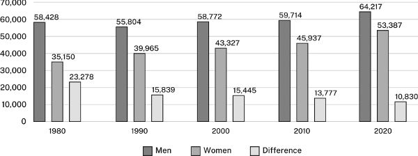

图 13.1. 1980 年至 2020 年男女工资差距的变化

Figure 13.1. Change in wage gap between men and women, 1980–2020

折线图显示随时间推移发生的连续变化：

A line graph suggests continuous change over time:

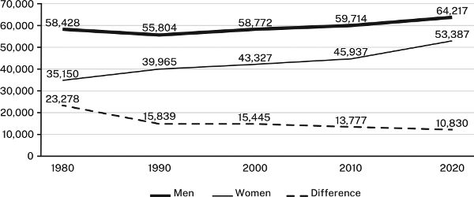

图 13.2. 1980 年至 2020 年男女工资差距的变化

Figure 13.2. Change in wage gap between men and women, 1980–2020

选择能达到预期效果的形式，而不是你首先想到的那种。如果你是定量研究新手，请将选择范围限制在基本表格、柱状图和折线图上。你的计算机软件可能提供了更多选择，但请忽略那些你不熟悉的选项。如果你正在进行高级研究，读者会期望你使用更多你所在领域常用的图表形式。在这种情况下，请参考表 13.6，其中描述了其他常用图表形式的修辞用途。如果你正在撰写一篇论文或文章，而该领域的研究经常涉及大型数据集中的复杂关系，那么你可能需要考虑更具创意的数据表示方法。（更多资源请参见附录。 ）

Choose the form that achieves the effect you want, not the one that first comes to mind. If you are new to quantitative research, limit your choices to basic tables, bar charts, and line graphs. Your computer software offers more choices, but ignore those you are not familiar with. If you are doing advanced research, readers will expect you to draw from a larger range of graphics favored in your field. In that case, consult table 13.6, which describes the rhetorical uses of other common forms. You may have to consider even more creative ways of representing data if you are writing a dissertation or article in a field that routinely displays complex relationships in large data sets. (See the appendix for additional resources.)

以下是表格、图表和图形的基础知识指南。

What follows is a guide to the basics of tables, charts, and graphs.

## 13.3 表格、图表和图形的设计

## 13.3 Designing Tables, Charts, and Graphs

演示软件可以制作出令人眼花缭乱的图形，以至于许多作者任由软件决定图形设计。这是个错误的做法。如果图形不能清晰地传达信息，读者根本不会在意它有多么精美。以下是一些设计有效图形的原则。

Presentation software can create graphics so dazzling that many writers let their software determine their design. That is a mistake. Readers don’t care how fancy a graphic is if it doesn’t communicate its point clearly. Here are some principles for designing effective graphics.

### 13.3.1 为每个图表添加边框，以帮助读者理解

### 13.3.1 Frame Each Graphic to Help Readers Understand It

用图表来展现复杂的数字关系，往往难以直接说明问题。你必须精心设计图表，让读者明白图表的内容以及它与你的论点之间的关联：

A graphic representing complex relationships among numbers rarely speaks for itself. You must frame it to show readers what to see in it and how to understand its relevance to your argument:

1. 1. 为每个图表添加标签，使其能够描述图表的数据。表格的标签称为标题*，*位于表格左上方；图形的标签称为*图例*， 位于图形左下方。标题和图例应简洁明了，但又要足够清晰，以便区分每个图表。
   - ▪ 避免将标题或图例设为一般性主题。

   > 注意：户主

   > 但是： 2005-2020年单亲家庭和双亲家庭户主的变化
   - ▪ 不要提供背景信息或描述数据所暗示的内容。

   > 注意： 2012-2022年，在工作人员专业化之前，咨询对抑郁症儿童的效果较弱

   > 但是：咨询对抑郁症儿童的影响，2012-2022 年
   - ▪ 确保标签能够区分呈现相似数据的图形。

   > 注意：高血压的风险因素

   > 但是：伊利诺伊州开罗市男性高血压的风险因素
2. 1. Label every graphic in a way that describes its data. For a table, the label is called a *title* and is set flush left above the table; for a figure, the label is called a *legend* and is set flush left below the figure. Keep titles and legends short but descriptive enough to distinguish every graphic from every other one.
   - ▪ Avoid making the title or legend a general topic.

   > NOT: Heads of households

   > BUT: Changes in one- and two-parent heads of households, 2005–2020
   - ▪ Do not give background information or characterize what the data imply.

   > NOT: Weaker effects of counseling on depressed children before professionalization of staff, 2012–2022

   > BUT: Effect of counseling on depressed children, 2012–2022
   - ▪ Be sure labels distinguish graphics presenting similar data.

   > NOT: Risk factors for high blood pressure

   > BUT: Risk factors for high blood pressure among men in Cairo, Illinois
3. 2. 在表格或图表中插入信息，帮助读者理解数据如何支持你的观点。例如，如果表格中的数字显示出某种趋势，而趋势的大小很重要，则在最后一列中标明变化幅度。如果图表中的某条线因图表中未提及的因素而发生变化，则在图表中添加文字进行解释。

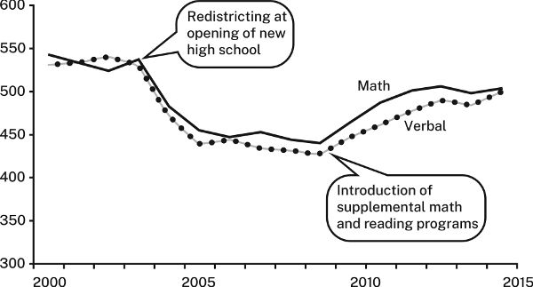

   图 13.3.中城高中 2000-2015 年 SAT 成绩

   > 1. 尽管重新划分学区后阅读和数学成绩下降了近 100 分，但当引入补充数学和阅读课程后，这一趋势发生了逆转。
   > 2. 3. 用一句话引出表格或图表，解释如何解读它。然后，重点突出表格或图表中你希望读者关注的内容，特别是引言中提到的任何数字或关系。例如，我们需要研究表 13.3，才能理解它如何支持前面的句子：
   > 3. 大多数关于汽油消耗量增加的预测都被证明是错误的。

   表 13.3. 1990-2020 年美国国内汽油需求量（单位：十亿加仑）

   |  | 1990 | 2000 | 2010 | 2020 |
   | --- | --- | --- | --- | --- |
   | 年消耗量 | 113.6 | 131.9 | 137.7 | 127.7 |

   我们需要一个更具信息量的标题，一句话来解释这些数字如何支持或说明论点，以及一些视觉提示来引导我们了解表格中应该看到的内容：
   > 1. 汽油消费量并未如预期般增长。在2000年代和2010年代，汽油消费量趋于平稳，甚至在2020年出现下降，这很可能是新冠疫情期间隔离措施的影响。
4. 2. Insert into the table or figure information that helps readers see how the data support your point. For example, if numbers in a table show a trend and the size of the trend matters, indicate the change in a final column. If a line on a graph changes in response to an influence not mentioned on the graph, add text to the image to explain it.

   Figure 13.3. SAT scores for Mid-City High, 2000–2015

   > 1. Although reading and math scores declined by almost 100 points following redistricting, that trend reversed when supplemental math and reading programs were introduced.
   > 2. 3. Introduce the table or figure with a sentence that explains how to interpret it. Then highlight what in the table or figure you want readers to focus on, particularly any number or relationship mentioned in that introductory sentence. For example, we have to study table 13.3 to understand how it supports the sentence before it:
   > 3. Most predictions about increased gasoline consumption have proved wrong.

   Table 13.3. US Domestic Demand for Gasoline, 1990–2020 (in billions of gallons)

   |  | 1990 | 2000 | 2010 | 2020 |
   | --- | --- | --- | --- | --- |
   | Annual consumption | 113.6 | 131.9 | 137.7 | 127.7 |

   We need a more informative title, a sentence to explain how the numbers support or illustrate the claim, and visual cues that guide us to what we should see in the table:
   > 1. Gasoline consumption has not grown as predicted. Through the 2000s and 2010s, gasoline consumption leveled off, and it even declined in 2020, likely as an effect of quarantining during the COVID-19 pandemic.

### 13.3.2 图形设计应尽可能简洁，与其内容相符

### 13.3.2 Keep All Graphics as Simple as Their Content Allows

有些指南鼓励你把尽可能多的数据塞进图表中。但读者只想看到与你的观点相关的数据，不想被其他信息分散注意力。所有图表都应遵循以下原则：

Some guides encourage you to cram as much data as you can into a graphic. But readers want to see only the data relevant to your point, free of distractions. For all graphics:

1. 1. 只包含相关数据。如果数据仅用于记录，请相应地标记并将其放在附录中。
2. 1. Include only relevant data. To provide data only for the record, label it accordingly and put it in an appendix.
3. 2. 保持视觉冲击力简洁。
   - ▪ 仅当两个或多个图形组合在一起时才需要用方框框住图形。
   - ▪ 不要给背景上色或添加阴影。
4. 2. Keep the visual impact simple.
   - ▪ Box a graphic only if you group two or more figures.
   - ▪ Do not color or shade the background.

表格

FOR TABLES

- ▪ 切勿同时使用水平和垂直的深色线条来分隔列和行。仅当表格结构复杂或您希望引导读者关注表格的行或列时，才可使用浅灰色线条。
- ▪ Never use both horizontal and vertical dark lines to divide columns and rows. Use light gray lines only if the table is complex or you want to focus your reader’s attention on its rows or its columns.
- ▪ 对于有很多行的表格，每隔五行涂上浅色阴影。
- ▪ For tables with many rows, lightly shade every fifth row.

图表和图形

FOR CHARTS AND GRAPHS

- ▪ 仅当图形复杂或读者需要查看精确数字时才使用背景网格线。网格线应为浅灰色。
- ▪ Use background grid lines only if the graphic is complex or readers need to see precise numbers. Make them light gray.
- ▪ 使用图案或阴影来区分对比。不要仅使用颜色或色调来区分对比，因为某些视力障碍人士可能无法分辨。尽可能使用图案或（更好的选择）标签。此外，如果您的图形之后将以黑白形式打印或复印，请避免使用颜色。
- ▪ Use patterns or shading to mark a contrast. Do not mark contrasts using colors or shades of color alone because people with certain visual impairments may not be able to distinguish them. Instead, rely on patterns or (better) labels wherever possible. Also, avoid using color if your graphic will be printed or photocopied in black-and-white later.
- ▪ 切勿为了追求视觉效果而使用图标式图表（例如，用汽车图片代表汽车产量）或三维立体图。这两种做法都显得不够专业，而且会扭曲读者对价值的判断。
- ▪ Never use iconic bars (for example, images of cars to represent automobile production) or three dimensions merely for effect. Both look amateurish and can distort how readers judge values.
- ▪ 仅当读者熟悉三维图表且无法以其他方式显示数据时，才绘制三维数据图。
- ▪ Plot data on three dimensions only when your readers are familiar with such graphs and you cannot display the data in any other way.
- 3. 使用清晰的标签。
  - ▪ 为表格中的所有行和列以及图表中的所有坐标轴添加标签。
  - ▪ 使用刻度线和标签来指示图表纵轴上的间隔。
  - ▪ 如果可能，请在图像上直接标注线条、柱状图段等，而不是使用侧边或下方的图例。只有当标注会使图像过于复杂而难以阅读时，才应使用图例。
  - ▪ 当需要关注具体数字时，可将其添加到图表中的柱状图或分段图，或添加到图形中的线条上的点。
- 3. Use clear labels.
  - ▪ Label all rows and columns in tables and both axes in charts and graphs.
  - ▪ Use tick marks and labels to indicate intervals on the vertical axis of a graph.
  - ▪ If possible, label lines, bar segments, and the like on the image rather than in a legend set to the side or below. Use a legend only if labels would make the image too complex to read easily.
  - ▪ When specific numbers matter, add them to bars or segments in charts or to dots on lines in graphs.

## 13.4 表格、柱状图和折线图的具体指南

## 13.4 Specific Guidelines for Tables, Bar Charts, and Line Graphs

### 13.4.1 表格

### 13.4.1 Tables

包含大量数据的表格可能会显得杂乱无章，因此要对其进行整理，以便于读者阅读。

Tables with lots of data can seem dense, so organize them to help readers.

- ▪ 行和列的排列顺序应遵循突出读者希望看到内容的原则。不要自动选择字母顺序。
- ▪ Order the rows and columns by a principle that emphasizes what you want readers to see. Do not automatically choose alphabetic order.
- ▪ 将数字四舍五入到合适的值。如果小于 1,000 的差异无关紧要，那么 2,123,499 的精确度就无关紧要了。
- ▪ Round numbers to a relevant value. If differences of less than 1,000 don’t matter, then 2,123,499 is irrelevantly precise.
- ▪ 总计位于列的底部或行的末尾，而不是顶部或左侧。
- ▪ Sum totals at the bottom of a column or at the end of a row, not at the top or left.

比较表13.4和表13.5：

Compare tables 13.4 and 13.5:

表13.4. 2000-2015年主要工业化国家的失业率

Table 13.4. Unemployment in major industrial nations, 2000–2015

[output not shown]

表 13.4看起来杂乱无章，各项内容的组织方式也不合理。相比之下，表 13.5则清晰得多，因为它标题信息丰富，视觉元素更少，而且各项内容的组织方式也便于我们更轻松地比较变化趋势。

Table 13.4 looks cluttered, and its items aren’t helpfully organized. In contrast, table 13.5 is clearer because it has an informative title, less visual clutter, and items organized to let us see the pattern of changes in comparative terms more easily.

表13.5. 2000-2015年工业化国家失业率变化

Table 13.5. Changes in unemployment rates of industrial nations, 2000–2015

|  | 2000 2000 | 2015 2015 | 改变 Change |
| --- | --- | --- | --- |
| 美国 United States | 9.6 9.6 | 6.2 6.2 | （3.4） (3.4) |
| 德国 Germany | 7.1 7.1 | 5.2 5.2 | （1.9） (1.9) |
| 英国 United Kingdom | 7.9 7.9 | 6.6 6.6 | （1.3） (1.3) |
| 加拿大 Canada | 8.0 8.0 | 6.9 6.9 | （1.1） (1.1) |
| 日本 Japan | 5.0 5.0 | 3.9 3.9 | （1.1） (1.1) |
| 瑞典 Sweden | 8.6 8.6 | 7.7 7.7 | （0.9） (0.9) |
| 澳大利亚 Australia | 5.2 5.2 | 6.2 6.2 | 1.0 1.0 |
| 法国 France | 9.7 9.7 | 10.7 10.7 | 1.0 1.0 |
| 意大利 Italy | 8.4 8.4 | 11.9 11.9 | 3.5 3.5 |

### 13.4.2 条形图

### 13.4.2 Bar Charts

条形图不仅通过具体的数字传递信息，也通过视觉冲击力来传达信息。但是，随意排列的条形图无法表达任何意义。如果可能，请将条形图分组并排列，以创建与信息相符的图像。例如，请结合图 13.4前面的说明文字来看一下。图中的条目是按字母顺序排列的，这种顺序不利于读者理解其含义：

Bar charts communicate as much by visual impact as by specific numbers. But bars arranged in no pattern imply no point. If possible, group and arrange bars to create an image that matches your message. For example, look at figure 13.4 in the context of the explanatory sentence before it. The items are listed alphabetically, an order that doesn’t help readers see the point:

> 世界上大部分沙漠集中在北非和中东地区。

> Most of the world’s deserts are concentrated in North Africa and the Middle East.

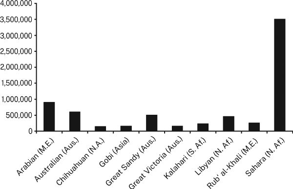

图 13.4世界十大沙漠

Figure 13.4. World’s ten largest deserts

相比之下，下一页的图 13.5用相应的图片支持了“世界上大部分沙漠集中在北非和中东”的说法。

In contrast, figure 13.5 on the next page supports the claim “Most of the world’s deserts are concentrated in North Africa and the Middle East” with a corresponding image.

· · ·

· · ·

在标准条形图中，每个条形代表整体的 100%。但有时读者需要查看整体各部分的具体数值。您可以通过两种方式提供这些数据：

In standard bar charts, each bar represents 100 percent of a whole. But sometimes readers need to see specific numbers for parts of the whole. You can provide them in two ways:

- ▪ 将条形图分成成比例的部分，形成“堆叠”条形图。
- ▪ Divide the bars into proportional parts, creating a “stacked” bar.
- ▪ 将整体的每个部分分别放在一个方框中，然后将各个部分分组。
- ▪ Give each part of the whole its own bar, then group the parts into clusters.

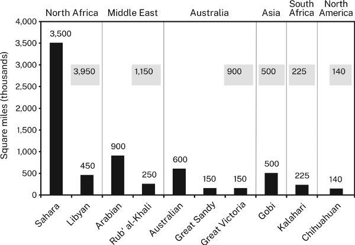

图 13.5.世界大型沙漠分布

Figure 13.5. World distribution of large deserts

只有当您希望读者比较不同柱状图的整体值而不是分割后的部分时，才应使用堆叠柱状图，因为读者仅凭肉眼很难比较各部分的比例。如果您确实要使用堆叠柱状图，请按以下步骤操作：

Use stacked bars only when you want readers to compare whole values for different bars rather than their divided segments, because readers can’t easily compare the proportions of segments by eye alone. If you do use stacked bars, do this:

- ▪ 将各线段按逻辑顺序排列。如果可能，将最大的线段放在最底部，并用最深的颜色标出。
- ▪ Arrange segments in a logical order. If possible, put the largest segment at the bottom in the darkest shade.
- ▪ 用特定数字标记各个线段，以便进行比较；用灰色线条连接相应的线段。
- ▪ Label segments with specific numbers to assist comparisons; connect corresponding segments with gray lines.

比较对面页的图 13.6和图13.7 。

Compare figures 13.6 and 13.7 on the facing page.

如果你因为认为片段和整体同样重要而将条形图分组，请这样做：

If you group bars because segments are as important as the wholes, do this:

- ▪ 按逻辑顺序排列各组；如果可能，将大小相似的条形放在一起（所有组中的条形排列方式相同）。
- ▪ Arrange groups in a logical order; if possible, put bars of similar size next to one another (order bars in the same way through all the groups).
- ▪ 在每个组上方或底部标签下方，用整体编号标记各组。
- ▪ Label groups with the number for the whole, either above each group or below the labels on the bottom.

大多数适合用条形图表示的数据也可以用饼图表示。饼图在杂志、小报和年度报告中很常见。饼图虽然色彩鲜艳，但比柱状图更难阅读。读者必须比较各个部分的比例，而这些部分的大小往往难以判断。不过，饼图也有其用武之地，尤其是在传达数据相对大小的定性印象时，例如，用来显示某个部分明显大于其他部分，或者显示数据整体大小不成比例地偏大。将饼图分成许多小部分。避免使用饼图来详细传达定量数据。为此，请使用柱状图。

Most data that fit a bar chart can also be shown in a pie chart. Pie charts are popular in magazines, tabloids, and annual reports. While splashy, they are harder to read than bar charts. Readers must compare proportions of segments whose sizes are often hard to judge. But pie charts have their place, especially to communicate qualitative impressions about the comparative size of data, either to show that one segment is disproportionately larger than the rest or that the data are divided into many small segments. Avoid using pie charts to convey quantitative data in any detail. For that, use bar charts.

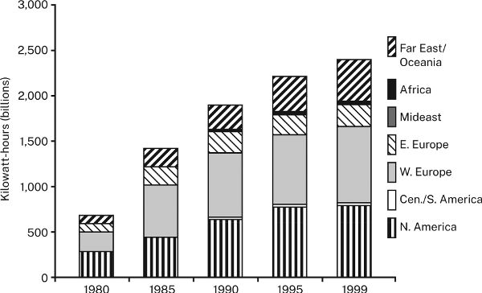

图 13.6. 1980-1999 年世界核能发电量

Figure 13.6. World generation of nuclear energy, 1980–1999

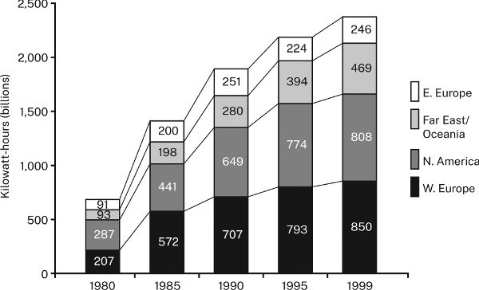

图 13.7. 1980–1999 年最大的核能发电厂

Figure 13.7. Largest generators of nuclear energy, 1980–1999

### 13.4.3 折线图

### 13.4.3 Line Graphs

由于折线图强调的是趋势，读者必须看到清晰的图像才能正确解读。请执行以下操作：

Because a line graph emphasizes trends, readers must see a clear image to interpret it correctly. Do the following:

- ▪ 选择能够使曲线朝支持你观点的方向（上升或下降）变化的变量。如果好消息是高中辍学率下降，你可以用一条上升的曲线来更有效地表示数据，表明留校率上升。如果你想强调坏消息，则需要找到一种方法将数据表示为一条下降的曲线。
- ▪ Choose the variable that makes the line go in the direction, up or down, that supports your point. If the good news is a reduction (down) in high school dropouts, you can more effectively represent the same data as a rising line indicating increase in retention (up). If you want to emphasize bad news, find a way to represent your data as a falling line.
- ▪ 只有当你无法用其他方式表达你的观点时，才可以在一张图上绘制超过六条线。
- ▪ Plot more than six lines on one graph only if you cannot make your point in any other way.
- ▪ 如果数据点少于十个左右，请用圆点表示。如果只有少数数据点相关，请插入数字以显示其确切值。
- ▪ If you have fewer than ten or so data points, indicate them with dots. If only a few are relevant, insert numbers to show their exact value.
- ▪ 不要依赖不同的灰色阴影来区分线条，如图13.8所示。
- ▪ Do not depend on different shades of gray to distinguish lines, as in figure 13.8.

比较对面页的图 13.8和图 13.9 。

Compare figure 13.8 and figure 13.9 on the facing page.

图 13.8难以阅读，因为灰色阴影无法很好地区分线条与背景，而且我们的目光需要来回移动才能将线条与图例联系起来。图 13.9则使这些联系更加清晰。

Figure 13.8 is harder to read because the shades of gray do not distinguish the lines well against the background and because our eyes have to flick back and forth to connect the lines to the legend. Figure 13.9 makes those connections clearer.

用不同的方式呈现相同的数据可能会令人困惑，因此请尝试不同的方案。制作不同的图表，然后请一位不熟悉数据的人来评判这些图表的冲击力和清晰度。务必在图表前附上一句话，阐明您希望它们支持的论点。

These different ways of showing the same data can be confusing, so test different options. Construct alternative graphics, then ask someone unfamiliar with the data to judge those alternatives for impact and clarity. Be sure to introduce the figures with a sentence that states the claim you want them to support.

## 13.5 以合乎伦理的方式表示数据

## 13.5 Representing Data Ethically

你的图表不仅要清晰准确，还要真实可信。不要为了论证观点而歪曲数据。例如，第230页上的两个柱状图虽然数据相同，却传达了不同的信息。

Your graphic must be not only clear and accurate, but honest. Do not distort the image of the data to make your point. On page 230, the two bar charts display identical data, yet imply different messages.

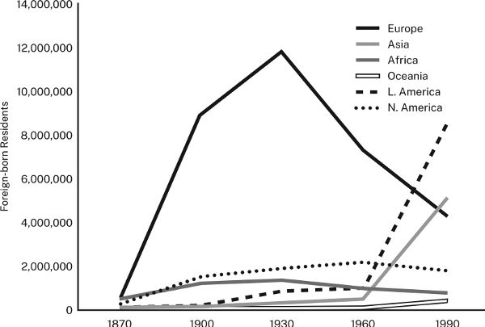

图 13.8. 1870–1990 年美国外国出生居民人数

Figure 13.8. Foreign-born residents in the United States, 1870–1990

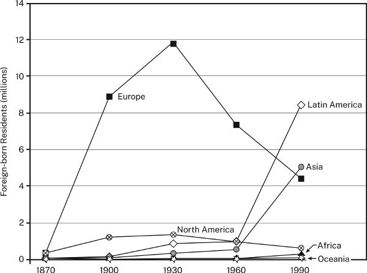

图 13.9. 1870–1990 年美国外国出生居民人数

Figure 13.9. Foreign-born residents in the United States, 1870–1990

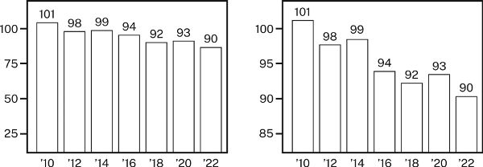

图 13.10.首府城市污染指数，2010–2022 年

Figure 13.10. Capitol City pollution index, 2010–2022

图 13.10 左侧的 0-100 刻度线形成了一个较为平缓的斜率，这使得污染下降的幅度看起来很小。然而，右侧的垂直刻度线并非从 0 开始，而是从 80 开始。当刻度线被如此截断时，会形成一个更陡峭的斜率，从而放大较小的差异。

The 0–100 scale on the left in figure 13.10 creates a fairly flat slope, which makes the drop in pollution seem small. The vertical scale on the right, however, begins not at 0 but at 80. When a scale is so truncated, it creates a sharper slope that exaggerates small contrasts.

图表也可能通过暗示虚假相关性而误导人。例如，有人可能会声称失业率随着工会会员人数的下降而下降，并以图 13.11作为证据。的确，在该图中，工会会员人数和失业率的变动似乎非常接近，以至于读者可能会推断出二者之间存在因果关系：

Graphs can also mislead by implying false correlations. Someone might claim that unemployment goes down as union membership goes down and offer figure 13.11 as evidence. And indeed, in that graph, union membership and the unemployment rate do seem to move together so closely that a reader might infer one causes the other:

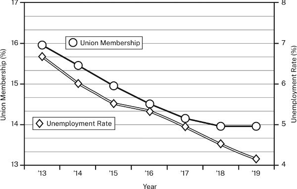

图 13.11. 2013-2019 年工会会员人数与失业率

Figure 13.11. Union membership and unemployment rate, 2013–2019

但是左轴（工会会员人数）的刻度与右轴（失业率）的刻度不同，这使得……两种趋势可能存在因果关系。它们或许确实存在因果关系，但这种扭曲的表象并不能证明这一点。

But the scale for the left axis (union membership) differs from the scale for the right axis (the unemployment rate), making it seem that the two trends could be causally related. They may be, but that distorted image doesn’t prove it.

图表也可能误导读者，让他们错误判断数值。图 13.12中的两张图表代表完全相同的数据，但似乎传达了不同的信息：

Graphs can also mislead when they encourage readers to misjudge values. The two charts in figure 13.12 represent exactly the same data but seem to communicate different messages:

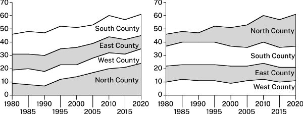

图 13.12. 1980-2020 年州立大学本科生中周边县的占比（占总数的百分比）

Figure 13.12. Representation of collar counties in state university undergraduates (percent of total), 1980–2020

图 13.12中的两个图表均为堆积面积图。这类图表并非通过线条的*角度，而是通过线条**之间的*面积来表示数值的变化。在两个图表中，南、东、西三个方向的条带宽度基本保持一致，表明它们所代表的数值变化不大。然而，北方向的条带则急剧变宽，表明其所代表的数值急剧增加。在左侧的图表中，读者很容易误判顶部三个条带的变化，因为它们位于不断上升的北方向条带之上，使得这些条带看起来也随之上升。而在右侧的图表中，这三个条带并没有上升，因为它们位于底部。此时，只有北方向的条带在上升。

The charts in figure 13.12 are both stacked area charts. Charts such as these represent changes in values not by the *angles* of the lines, but by the areas *between* them. In both charts, the bands for south, east, and west are roughly the same width throughout, indicating little change in the values they represent. The band for the north, however, widens sharply, representing a sharp increase in the numbers it represents. In the chart on the left, readers could easily misjudge the top three bands, because they are on top of the rising north band, making those bands seem to rise as well. In the chart on the right, on the other hand, those three bands do not rise because they are on the bottom. Now only the band for the north rises.

以下是避免视觉误导的四条准则：

Here are four guidelines for avoiding visual misrepresentation:

- ▪ 请勿通过调整标尺来放大或缩小对比度。
- ▪ Do not manipulate a scale to magnify or reduce a contrast.
- ▪ 不要使用图像会扭曲数值的图形。
- ▪ Do not use a figure whose image distorts values.
- ▪ 不要使表格或图表过于复杂或过于简单而具有误导性。
- ▪ Do not make a table or figure unnecessarily complex or misleadingly simple.
- ▪ 如果表格或图表支持某个观点，请说明。
- ▪ If the table or figure supports a point, state it.

表 13.6.常见图形及其用途

Table 13.6. Common graphic forms and their uses

| 数据 Data | 修辞手法 Rhetorical Uses |
| --- | --- |

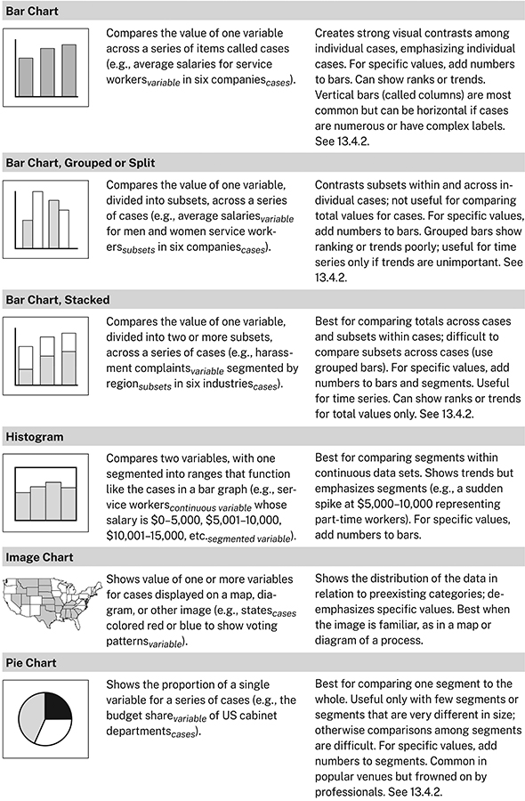

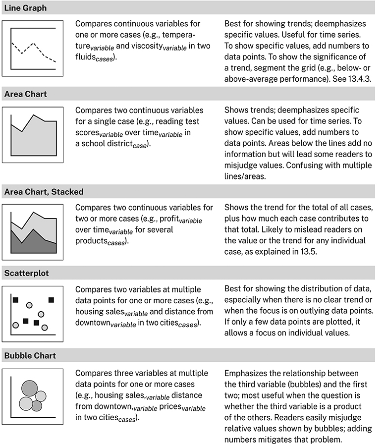

▶ 小贴士：寻找机会加入视觉证据

▶ Quick Tip: Look for Opportunities to Include Visual Evidence

如今，各领域的论文和演示文稿越来越多地采用多模态形式——即包含视觉信息和文字信息。多模态论证在自然科学和许多社会科学领域早已司空见惯，并且正逐渐被传统上避免使用多模态的领域所接受。因此，初级研究人员比以往任何时候都更需要学习如何以及何时以图形形式（而非仅以文字形式）呈现数据或信息。即使您的论文或演示文稿不需要*视觉*证据，但添加视觉证据也可能有所助益，因为多种证据呈现方式协同作用，能提高听众理解并接受您论点的可能性。所以，请留意以视觉方式呈现数据的机会：

Increasingly, papers and presentations in all fields are multimodal—that is, they include visual as well as verbal information. Multimodal arguments have long been the norm in the natural sciences and many social sciences and are becoming accepted in fields that have traditionally avoided them. More than ever then, beginning researchers must learn how and when to present data or information in graphic form, rather than in words alone. Even if your paper or presentation doesn’t *need* visual evidence, it might benefit from having it because multiple modes of representing evidence, working together, make it more likely that your audience will understand and be convinced by your arguments. So be on the lookout for opportunities to represent that data visually:

- ▪ **注意你所在领域的资料是如何使用视觉证据的。**不仅要注意呈现的数据或信息的类型，还要注意这些呈现形式。
- ▪ **Notice how sources in your field use visual evidence.** Pay attention not just to the kinds of data or information that get represented but to the forms those representations take.
- ▪ **向经验丰富的研究人员请教他们在自己的研究中如何使用视觉证据。**当你了解专家们的选择时，你也能做出更好的选择。
- ▪ **Ask experienced researchers how they use visual evidence in their own work.** When you understand the choices experts make, you will make better choices yourself.
- ▪ **决定在论文中至少使用一张图表。**仅此一项决定就能让你专注于如何在论证中使用视觉证据。
- ▪ **Decide to use at least one graphic in your paper.** That decision alone will focus your attention on ways you can use visual evidence in your argument.
- ▪ **向老师询问是否有需要使用视觉证据的作业。**大多数老师都乐于看到学生在自己的作品中借鉴和借鉴他们从资料中看到并欣赏的做法。即使作业没有明确要求使用图表，也不要不好意思向老师询问是否可以这样做。
- ▪ **Ask your teachers for assignments that invite the use of visual evidence.** Most teachers appreciate it when students aspire to make moves in their own work that they see and admire in their sources. Even if your assignment doesn’t explicitly call for you to use graphics, don’t be shy about asking your teachers for the option to do so.

# 14 引言和结论

# 14 Introductions and Conclusions

好的引言能激发读者的兴趣，帮助他们更好地理解你的作品。好的结论则能清晰地阐明你的观点，并加深读者对作品意义的理解。本章将教你如何撰写引言和结论。你花在引言和结论上的时间或许是你写作中最宝贵的。

A good introduction encourages readers to read your work with interest and prepares them to understand it better. A good conclusion leaves them with a clear statement of your point and renewed appreciation of its significance. In this chapter, we show you how to write both. The time you spend on your introduction and conclusion may be your most important.

一旦你觉得草稿已经可以接受，就可以着手撰写最终的引言和结论了。有些作者认为这意味着遵循老生常谈的建议：*用一些简洁明了或引人入胜的文字吸引读者的注意力。*这条建议并非毫无用处，但你的读者想要的远不止这些。在第一部分中，我们向你展示了如何围绕一个研究问题展开项目。在这里，我们将向你展示如何利用这个问题来吸引读者。一个吸引人的开头或许能激发读者的注意力，但真正能留住他们的，是他们认为需要解决的问题，以及你已经找到解决方案的承诺。正如我们所说，你可以与那些说“*我不同意”的读者沟通。但对于那些耸耸肩说**“我不在乎”*的人，你却无能为力。

Once you think you have a draft that works, you’re ready to write your final introduction and conclusion. Some writers think that means following the standard advice: *Grab their attention with something snappy or cute.* That advice is not useless, but your audience wants more than cute and snappy. In part I, we showed you how to develop a project around a research problem. Here, we show you how to use that problem to engage your audience. A catchy opening might spark readers’ attention, but what keeps their attention is a problem they think needs a solution and a promise that you have found it. As we have said, you can always work with readers who say, *I don’t agree.* You can’t do much with those who shrug and say, *I don’t care.*

## 14.1 引言的常见结构

## 14.1 The Common Structure of Introductions

正如我们所指出的，不同的研究群体开展工作的方式各不相同。虽然它们表面上的介绍可能有所不同，但其内在结构却是相同的。请看以下三个分别来自文化批评、计算机设计和法律史领域的简要示例：

As we have noted, different research communities do things in different ways. While their introductions may look different on the surface, their underlying structures are the same. Consider these three condensed examples from the fields of cultural criticism, computer design, and legal history:

> （1）为什么机器不能更像人？在*《星际迷航：下一代》的几乎每一集中，*机器人Data都在思考是什么造就了人。在最初的《星际*迷航》中，半瓦肯人斯波克先生也提出了*类似的问题，他作为人的地位也受到了质疑。他那如同机器般的逻辑和情感的缺失，使他显得冷漠无情。事实上，Data和Spock只是众多探索人性本质的“准人类”中的两个例子。从弗兰肯斯坦的怪物到终结者，各种各样的生物都曾被提出过类似的问题。但真正的问题是，为什么这些努力成为“人”的角色几乎总是白人男性？作为文化诠释者，他们是否在潜移默化地强化了关于“正常”的有害刻板印象？理想人格的构建似乎实际上是由西方标准决定的，而这些标准将世界上绝大多数人排除在外。

> (2) 作为持续质量改进 (CQI) 项目的一部分，Motodyne Computers 计划重新设计其 Unidyne™<sup>在线</sup>帮助系统的用户界面。该界面规范要求使用能够让用户无需文字说明即可识别其功能的自解释性图标。Motodyne 已使用其现有图标集三年，但没有数据表明哪些图标是自解释性的。由于缺乏此类数据，我们无法确定需要重新设计哪些图标。本报告提供了 11 个图标的数据，结果表明其中 5 个图标并非自解释性的。

> （3）在当今社会，1780年在美军后方被俘的英国便衣间谍约翰·安德烈少校会被处以绞刑吗？尽管他被视为一位高尚的爱国者，但他还是受到了军事法律规定的惩罚。随着时间的推移，我们的传统发生了变化，但间谍罪的惩罚却未变。它是唯一一项必须判处死刑的罪行。然而，最近最高法院驳回了民事案件中强制执行死刑的判例，这使得死刑在军事案件中的适用变得模糊不清。如果最高法院的判决适用于军事领域，国会是否需要修订《统一军事司法法典》？本文的结论是肯定的。

> (1) Why can’t a machine be more like a man? In almost every episode of *Star Trek: The Next Generation*, the android Data wonders what makes a person a person. In the original *Star Trek*, similar questions were raised by the half-Vulcan Mr. Spock, whose status as a person was undermined by his machinelike logic and lack of emotion. In fact, Data and Spock are only two examples of “quasi-persons” who have explored the nature of humanity. The same question has been raised by and about creatures ranging from Frankenstein’s monster to the Terminator. But the real question is why these characters who struggle to be persons are almost always white and male. As cultural interpreters, do they tacitly reinforce destructive stereotypes of what it means to be “normal”? The model person seems in fact to be defined by Western criteria that exclude most of the people in the world.

> (2) As part of its program of Continuous Quality Improvement (CQI), Motodyne Computers plans to redesign the user interface for its Unidyne<sup>TM</sup> online help system. The specifications for its interface call for self-explanatory icons that let users identify their function without verbal labels. Motodyne has three years’ experience with its current icon set, but it has no data showing which icons are self-explanatory. Lacking such data, we cannot determine which icons to redesign. This report provides data for eleven icons, showing that five of them are not self-explanatory.

> (3) In today’s society, would Major John André, a British spy in civilian clothes captured behind American lines in 1780, be hanged? Though considered a noble patriot, he suffered the punishment mandated by military law. Over time our traditions have changed, but the punishment for spying has not. It is the only offense that mandates death. Recently, however, the Supreme Court has rejected mandatory death sentences in civilian cases, creating an ambiguity in their application to military cases. If Supreme Court decisions apply to the military, will Congress have to revise the Uniform Code of Military Justice? This article concludes that it will.

这三篇导论所提出的主题和问题与其目标读者群体一样各不相同，但它们背后却隐藏着一个共同的模式，读者无论在哪个领域，都会在所有导论中寻找这种模式。这种共同的结构包含三个要素：

The topics and problems posed in those three introductions differ as much as their intended audiences, but behind them is a shared pattern that readers look for in all introductions, regardless of field. That common structure consists of three elements:

- ▪ 上下文陈述
- ▪ statement of the context
- 问题陈述
- ▪ statement of the problem
- ▪ 回应声明
- ▪ statement of a response

并非每篇介绍都包含这三个要素，但大多数都包含。

Not every introduction has all three elements, but most do.

以下是每篇引言*中“背景+问题+回应”*的模式：

Here is that pattern of *context + problem + response* in each of those introductions:

> （1）背景：为什么机器不能更像人呢？……从弗兰肯斯坦的怪物到终结者，各种各样的生物都曾被提出过同样的问题。

> 问题：但真正的问题是……它们是否在潜移默化中强化了关于“正常”含义的有害刻板印象？

> 回应：事实上，理想人物的定义似乎是由西方标准决定的，而这排除了世界上大多数人。

> (1) CONTEXT: Why can’t a machine be more like a man? . . . The same question has been raised by and about creatures ranging from Frankenstein’s monster to the Terminator.

> PROBLEM: But the real question is . . . do they tacitly reinforce destructive stereotypes of what it means to be “normal”?

> RESPONSE: The model person seems in fact to be defined by Western criteria that exclude most of the people in the world.

> （2）背景：作为持续质量改进（CQI）计划的一部分，Motodyne Computers公司计划重新设计用户界面……Motodyne公司使用其现有图标集已有三年经验……

> 问题： ……但它没有数据表明哪些图标是无需解释的。由于缺乏此类数据，我们无法确定需要重新设计哪些图标。

> 回复：本报告提供了 11 个图标的数据，表明其中 5 个图标的含义并不明确。

> (2) CONTEXT: As part of its program of Continuous Quality Improvement (CQI), Motodyne Computers plans to redesign the user interface. . . . Motodyne has three years’ experience with its current icon set . . .

> PROBLEM: . . . but it has no data showing which icons are self-explanatory. Lacking such data, we cannot determine which icons to redesign.

> RESPONSE: This report provides data for eleven icons, showing that five of them are not self-explanatory.

> （3）背景：在当今社会，约翰·安德烈少校会因为间谍罪被绞死吗？……这是唯一一种会被判处死刑的罪行。

> 问题：然而，最高法院最近驳回了民事案件中强制执行死刑的判例，这使得死刑在军事案件中的适用变得模糊不清……国会是否需要修订《统一军事司法法典》？

> 回应：本文的结论是，它将会发生。

> (3) CONTEXT: In today’s society, would Major John André . . . be hanged [for spying]? . . . It is the only offense that mandates death.

> PROBLEM: Recently, however, the Supreme Court has rejected mandatory death sentences in civilian cases, creating an ambiguity in their application to military cases. . . . [W]ill Congress have to revise the Uniform Code of Military Justice?

> RESPONSE: This article concludes that it will.

这些要素各自发挥着作用，既能激发读者阅读论文的兴趣，又能帮助他们理解论文的内容。

Each of those elements plays its own role in motivating readers to read your paper and in helping them to understand it.

## 14.2 第一步：陈述背景

## 14.2 Step 1: Stating a Context

想象一下童话故事的开头：

Consider the opening of a fairy tale:

> 在一个阳光明媚的早晨，小红帽蹦蹦跳跳地穿过森林，前往奶奶家。<sub>[想象一下，蝴蝶在她头顶翩翩起舞，伴随着笛声和小提琴声]</sub>

> One sunny morning Little Red Riding Hood was skipping through the forest on her way to Grandmother’s house.<sub>stable context [imagine butterflies dancing around her head to flutes and violins]</sub>

就像大多数童话故事的开头一样，这个故事也建立了一个稳定甚至幸福的背景，只是为了让这种氛围被一个问题打破：

Like the opening to most fairy tales, this one establishes a stable, even happy context, just so that it can be disrupted with a problem:

> ……突然，饿狼从树后跳了出来，<sub>打破了平静（想象一下长号和低音号齐鸣），</sub>吓坏了她（如果孩子们沉浸在故事里，也会被吓到）。<sub>成本</sub>

> . . . when suddenly Hungry Wolf jumped out from behind a tree<sub>disrupting condition [imagine trombones and tubas]</sub> frightening her [and, if they’ve lost themselves in the story, little children as well].<sub>cost</sub>

故事的其余部分详细阐述了这个问题，然后解决了这个问题。

The rest of the story elaborates that problem and then resolves it.

大多数引言都遵循相同的策略。为了建立*共同基础*——即读者和作者对作者将要探讨的更广泛议题的共同理解——它们会先陈述一个*稳定的背景，*一些看似毫无争议的、已被人们熟知或接受的事物。然后，作者会提出一个问题来打破这种稳定，实际上是在说：*读者，你或许认为自己了解某些事情，* 但 *你的知识并不完善或完整。*

Most introductions follow the same strategy. To establish *common ground*—a shared understanding between audience and writer about the larger issue the writer will address—they state a *stable context*, some apparently unproblematic account of what is already known or accepted. The writer then disrupts it with a problem, saying in effect: *Reader, you may think you know something,* but *your knowledge is imperfect or incomplete.*

> （3）稳定 背景：在当今社会，英国间谍约翰·安德烈少校会被处以绞刑吗？……间谍活动是唯一会被判处死刑的罪行。

> 棘手 问题：**然而**，最近最高法院驳回了强制性死刑判决……

> (3) STABLE CONTEXT: In today’s society, would Major John André, a British spy . . . be hanged? . . . [Spying] is the only offense that mandates death.

> DISRUPTING PROBLEM: Recently, **however**, the Supreme Court has rejected mandatory death sentences. . . .

当作者确信读者已经意识到他们提出的问题*是一个问题时，*他们有时会省略背景介绍，这通常是因为该问题在特定的研究领域内已被广泛认可。而这篇引言则直接以一个问题开篇：

Writers sometimes skip the context when they are sure their readers already recognize their problem *as a problem*, usually because it is well established in a particular research community. This introduction opens directly with a problem:

> 最新的科学模型预测，海平面上升将在本世纪末之前对世界沿海城市构成威胁。

> The most recent scientific models predict that rising sea levels will threaten the world’s coastal cities well before the end of this century.

但通常情况下，读者需要一些背景信息才能理解问题的意义，因此作者会用看似无关紧要的细节来引出问题。在既定认知或先前研究的背景下，*他们尤其希望能够颠覆这种*认知或研究：

But usually, readers need some context to understand a problem’s significance, so writers introduce it with the seemingly unproblematic context of an accepted understanding or prior research, *specifically so they can disrupt it*:

> 由于他汀类药物能有效降低胆固醇且副作用似乎很小，长期以来一直被用作预防心血管疾病和中风的常规药物。然而，2010年代进行的几项研究表明，他汀类药物可能会增加认知障碍和痴呆的风险，导致<sub>医学界对其广泛使用</sub><sub>产生一些疑虑。</sub>

> Because of their effectiveness in lowering cholesterol and seemingly minor side effects, statins have long been prescribed as a routine preventative treatment for cardiovascular disease and strokes.<sub>stable context</sub> However, several studies conducted in the 2010s suggested that statins may increase risk of cognitive impairment and dementia,<sub>destabilizing condition</sub> leading to some uncertainty in the medical community about their widespread use.<sub>consequence</sub>

现在读者对这个问题感兴趣的理由不止一个，而是两个：不仅是问题本身，还有他们对整个问题的理解还不够全面。

Readers now have not one reason to be interested in the problem, but two: not just the problem itself, but also their incomplete understanding of the whole matter.

你的描述可能表明存在误会：

Your context can describe a misunderstanding:

> **人们普遍认为十字军东征的动机是出于宗教热情，目的是将圣地归还基督教世界。**<sub>但事实上</sub> **，**其动机至少部分是政治性的，即便不是主要政治性的。

> **The Crusades are widely believed to have been motivated by religious zeal to restore the Holy Land to Christendom.**<sub>stable context</sub> **In fact,** the motives were at least partly, if not largely, political.

它可以调查过时的认知或研究：

It can survey obsolete understandings or research:

> **很少有社会学概念像“宗教信仰能预防自杀”这一观点那样迅速地被人们遗忘。它曾是社会学的基本信条之一，但近期的一系列研究对其提出了质疑……**<sub>稳定的背景。</sub> **然而**，某些研究仍然发现宗教对自杀有一定影响……

> **Few sociological concepts have fallen out of favor as fast as the notion that religious faith provides a protective influence against suicide. Once one of sociology’s basic beliefs, it has been called into question by a series of recent studies. . . .**<sub>stable context</sub> **However,** certain studies still find an effect of religion . . .

或者，这可能表明人们对问题本身存在误解：

Or it can point to a misunderstanding about the problem itself:

> **美国教育一直注重培养孩子的批判性思维能力，鼓励他们提出问题并检验答案。****然而，**批判性思维领域却被各种时尚潮流和特殊利益集团所主导。

> **American education has focused on teaching children to think critically, to ask questions and test answers.**<sub>stable context</sub> **But** the field of critical thinking has been taken over by fads and special interests.

一些经验不足的研究者忽略了背景信息，论文开头就像是在课堂上接着刚才的讨论继续写一样。他们的引言非常简略，只有班上的其他同学才能看懂。

Some inexperienced researchers skimp on context, opening their papers as if they were picking up a class conversation where it left off. Their introductions are so sketchy that only others in the course would understand them:

> 鉴于霍夫斯塔特未能尊重数学、音乐和艺术之间的差异，他的*《具身心智》一书*引发的强烈反响也就不足为奇了。然而，这场争议的起因却不太明朗。我认为，任何对人类心智的解释都必须是跨学科的……

> In view of Hofstadter’s failure to respect the differences among math, music, and art, it is not surprising that the response to *The Embodied Mind* would be stormy. It is less clear what caused the controversy. I will argue that any account of the human mind must be interdisciplinary. . . .

在撰写引言时，想象你是在给一位读过和你一样的资料、对同样的问题也比较感兴趣的人写信，但这位读者并不知道你的课堂上具体发生了什么。

When you draft your introduction, imagine you are writing to someone who has read some of the same sources as you and is generally interested in the same issues, but does not know what specifically happened in your class.

另一些人则犯了相反的错误，认为应该列出所有与主题略有相关的文献资料。实际上，只需查阅那些你会*直接*修改其结论的文献即可。只有当你需要将问题置于更广泛的背景下进行探讨时，才应添加更多文献。

Others make the opposite mistake, thinking they should list every source they read that remotely touches their topic. Survey only those sources whose findings you will *directly* modify. Add more only if you need to locate the problem in a wider context.

## 14.3 步骤 2：陈述你的问题

## 14.3 Step 2: Stating Your Problem

一旦你确定了一个稳定的背景，就用一个问题来打破它（参见第二章）。正如我们所说，研究问题的陈述包含两个部分：

Once you state a stable context, disrupt it with a problem (see chapter 2). As we have said, the statement of a research problem has two parts:

- ▪知识或理解不完整的*状态*，以及
- ▪ a *condition* of incomplete knowledge or understanding, and
- ▪这种情况*的后果*，以及由此造成的理解上的更大差距
- ▪ the *consequences* of that condition, a more significant gap in understanding

您可以直接陈述条件：

You can state the condition directly:

> ……但 Motodyne 没有数据显示哪些图标是不言自明的。

> . . . but Motodyne has no data showing which icons are self-explanatory.

或者，你也可以用间接提问的方式来暗示：

Or you can imply it in an indirect question:

> 真正的问题是，为什么这些角色几乎总是白人男性。

> The real question is why these characters are almost always white and male.

*只有当你设想有人会问“那又怎样？”*，然后详细阐述这种无知或理解偏差的后果时，你才能将这种状况视为一个完整的研究问题*。*你可以将这种后果表述为直接成本：

You make this condition of ignorance or flawed understanding part of a full research problem only when you imagine someone asking, *So what?*, and then spell out as an answer that condition’s *consequence*. You can state that consequence as a direct cost:

> 由于缺乏此类数据，我们无法确定需要重新设计哪些图标。<sub>成本</sub>

> Lacking such data, we cannot determine which icons to redesign.<sub>cost</sub>

或者，你可以将成本转化为收益：

Or you can transform the cost into a benefit:

> 有了这些数据，我们就可以确定需要重新设计哪些图标<sub>。</sub>

> With such data, we could determine which icons to redesign.<sub>benefit</sub>

列举成本还是列举收益并非仅仅是风格问题。读者通常更容易被实际成本而非潜在收益所吸引。我们的建议是：在阐述问题时列举成本或后果；在阐述解决方案时列举收益，以增强其说服力。

The choice between stating a cost and stating a benefit is not just a matter of style. Readers are typically more motivated by a real cost than by a potential benefit. Our suggestion: state costs or consequences when presenting your problem; state benefits to intensify your solution.

这是陈述问题的标准方式，但还有其他选择。

That’s the standard way to state a problem, but there are options.

### 14.3.1 是否应该明确陈述问题的条件？

### 14.3.1 Should You State the Condition of a Problem Explicitly?

有时，你会遇到一些非常熟悉的问题，以至于它的名称本身就暗示了该领域人士所面临的条件和后果：例如， *DNA 在人格中的作用；**莎士比亚*的语言能力。同样，在数学和自然科学等一些领域，许多研究问题广为人知，因此只需说明其条件，就能让人联想到其后果。以下是对克里克和沃森关于 DNA 双螺旋结构的里程碑式论述的（简略）介绍：

Occasionally, you tackle a problem so familiar that its name implies both its condition and consequence to those in the field: *the role of DNA in personality*; *Shakespeare’s knowledge of languages*. Likewise, in some fields like mathematics and the natural sciences, many research problems are widely known, so just stating the condition is enough to bring to mind its consequence. Here again is that (condensed) introduction to Crick and Watson’s landmark account of the double-helix structure of DNA:

> 我们希望提出一种脱氧核糖核酸（DNA）盐的结构。该结构具有一些新颖的特征，具有重要的生物学意义。鲍林和科里此前已提出过一种核酸结构。他们慷慨地在发表前将手稿提供给了我们。他们的模型由三条相互缠绕的链组成，磷酸基团靠近纤维轴，碱基位于外侧。我们认为，这种结构并不令人满意……

> We wish to suggest a structure for the salt of deoxyribose nucleic acid (D.N.A.). This structure has novel features which are of considerable biological interest. A structure for nucleic acid has already been proposed by Pauling and Corey. They kindly made their manuscript available to us in advance of publication. Their model consists of three intertwined chains, with the phosphates near the fibre axis, and the bases on the outside. In our opinion, this structure is unsatisfactory. . . .

他们只需“提出”一种DNA结构就足够了，因为他们知道每个人都想知道它到底是什么。（不过需要注意的是，他们也提出了一个问题，那就是他们提到了鲍林和科里提出的*错误*模型。）

It was enough for them merely to “suggest” a structure for DNA, because they knew everyone wanted to know what it was. (Note, though, that they do raise a problem by mentioning Pauling and Corey’s *incorrect* model.)

在自然科学和大多数社会科学领域，研究人员通常会探讨读者熟悉的问题。在这些领域，你或许认为无需详细阐述你的研究问题。但如果你不告诉读者，他们就无法了解你的研究将填补他们知识体系中的哪个空白。

In the natural sciences and most social sciences, researchers usually address questions familiar to their readers. In these fields, you might think you do not need to spell out your problem. But readers will not know the particular gap in their knowledge that your research will fill unless you tell them.

在人文科学和某些社会科学领域，研究者常常提出他们自己发现甚至创造的问题，这些问题对读者来说新颖且往往出人意料。在这些领域，你必须明确描述你打算弥补的理解上的不足或不完整之处。

In the humanities and some social sciences, researchers more often pose questions that they alone have found or even invented, questions that readers find new and often surprising. In these fields, you must explicitly describe the imperfect or incomplete understanding that you intend to remedy.

### 14.3.2 是否应该说明后果和好处？

### 14.3.2 Should You State Consequences and Benefits?

要想让读者认真对待你的问题，他们必须意识到问题不解决会给*他们带来哪些损失，或者问题解决会给**他们*带来哪些好处。如果这些损失和好处显而易见，不仅对你而言如此，对读者也是如此，那么你可以省略它们。但如果并非如此，你就需要明确地说明它们。如有任何疑问，请务必说明。

For readers to take your problem seriously, they must recognize the cost *they* will pay if it is not resolved or the benefits *they* will gain if it is. When these costs and benefits are obvious, not just for you but for your readers, you may omit them. But if not, you need to make them explicit. If in doubt, state them.

有时你可以描述你的研究如何帮助读者避免实际成本：

Sometimes you can describe tangible costs that your research helps your readers avoid:

> 去年，河城监事会同意将海湾开发项目纳入河城的税基。然而，他们的计划缺乏经济分析。如果监事会在不了解成本的情况下投票决定吞并海湾开发项目，则**可能加剧河城本已岌岌可危的财政状况。**如果将污水和供水服务升级到符合城市标准的负担纳入分析，吞并的成本将远超监事会的预期。

> Last year the River City Supervisors agreed that River City should add the Bayside development to its tax base. Their plan, however, was based on little economic analysis. If the Board votes to annex Bayside without understanding what it will cost the city, **the Board risks worsening River City’s already shaky fiscal situation.** When the burden of bringing sewer and water service up to city code are included in the analysis, the annexation will cost more than the Board assumes.

*这就是引入应用*研究问题的方法，其中知识的匮乏（缺乏经济分析）会造成切实的后果（更高的成本）。而引入纯粹研究问题时，你无需用金钱等具体术语来解释后果，而是将其描述为误解，或者，更深入的理解可能带来的益处：

This is how to introduce a problem of *applied* research, in which the area of ignorance (no economic analysis) has tangible consequences (higher costs). To introduce a problem of pure research, you explain the consequence not in tangible terms such as money but as misunderstanding or, alternatively, as the possible benefit of better understanding:

> 几十年来，美国城市为了扩大税基，不断吞并高档社区，但往往收效甚微，经济效益却不尽如人意。然而，如果当初进行一些基本的经济分析，这些结果本可以预见。吞并运动正是地方政治决策未能有效利用专家信息的典型案例。令人费解的是，为什么城市不寻求这些专家的意见。**如果我们能够探究城市为何不依赖基本的经济分析，或许就能更好地理解它们在其他领域的决策为何也屡屡失败。**本文分析了三个城市在未考虑经济后果的情况下吞并周边地区的决策过程。

> For decades, American cities have annexed upscale neighborhoods to prop up tax bases, often bringing disappointing economic benefits. But those results could have been predicted had they done basic economic analysis. The annexation movement is a case study of how political decisions at the local level fail to use expert information. What is puzzling is why cities do not seek out that expertise. **If we can discover why cities fail to rely on basic economic analyses, we might better understand why their decision-making fails so often in other areas as well.** This paper analyzes the decision-making process of three cities that annexed surrounding areas without consideration of economic consequences.

### 14.3.3 测试条件和后果

### 14.3.3 Testing Conditions and Consequences

在第二章中，我们提出了一种方法来测试你是否能清晰地阐述不解决问题的后果：在最能说明问题的句子之后。指出读者的无知或误解，然后问：*那又怎样？*

In chapter 2, we suggested a way to test how clearly you articulate the consequences of not solving a problem: after the sentences that best state your readers’ condition of ignorance or misunderstanding, ask, *So what?*

> Motodyne公司没有数据表明哪些图标是无需解释的。[*那又怎样？* ] 没有这些数据，它就无法确定需要重新设计哪些图标。

> 20 世纪 80 年代及之后，人们对二战时期人物“铆钉女工罗西”的兴趣重新燃起，这表明一个标志性形象可以被赋予新的政治和文化意义，而事后看来，我们也承认这些意义具有排他性。

> 那*又怎样？*嗯……

> Motodyne has no data showing which icons are self-explanatory. [*So what?*] Without such data, it cannot determine which icons to redesign.

> The resurgent interest in the World War II–era figure Rosie the Riveter in the 1980s and after shows how an iconic image may be turned to new political and cultural ends that in retrospect we acknowledge as also exclusionary.

> [*So what?*] Well . . .

*“那又怎样？”*这种回答有时会让人恼火。如果你喜欢“铆钉女工罗西”的图片，你可以尽情欣赏而无需向任何人解释；但如果你想让别人认可你对这方面的兴趣，并将其视为一种研究，你就必须让他们明白它的意义所在。

Answering *So what?* can be exasperating. If you like images of Rosie the Riveter, you can explore them without answering to anyone, but if you want others to appreciate this interest as research, you have to “sell” them on its significance.

要想让观众关心这个问题，你必须让他们明白，你的问题就是*他们的*问题——即使他们现在还没意识到。你必须让他们相信，了解二战时期“铆钉女工罗西”的形象如何在20世纪80年代被重塑为女权主义偶像，并在本世纪被公认为白人女性赋权的象征，将有助于他们理解一些更重要的东西：*文化*身份是如何形成和变迁的*，以及*我们自身认知的局限性。

To convince an audience to care, you have to show them that your problem is *their* problem—even if they don’t know it yet. You have to convince them that learning how the World War II–era figure of Rosie the Riveter was recast as a feminist icon in the 1980s and then later—in this century—recognized as a symbol of specifically white women’s empowerment will help them understand something more important *both* about how cultural identities are formed and changed *and* about the partiality of our own understanding.

当然，有些听众会再次质疑：“*那又怎样？我不在乎文化认同。”*对此，你只能说：“找*错听众了。”*成功的研究人员不仅知道如何发现并解决有趣的问题，他们也知道如何找到（或创造）对他们所解决的问题感兴趣的受众。

To be sure, some audiences will ask again, *So what? I don’t care about cultural identities.* To which you can only say, *Wrong audience.* Successful researchers know how to find and solve interesting problems, but they also know how to find (or create) an audience interested in the problems they solve.

如果你确信你的听众了解你提出的问题所带来的后果，你或许可以决定不明确指出这些后果。克里克和沃森并没有具体说明不了解DNA结构的代价，因为他们知道听众已经意识到，如果不了解DNA结构，就无法理解遗传学（这才是更重要的东西）。如果克里克和沃森把这个后果说得那么清楚，可能会显得多余或居高临下。

If you are sure your audience knows the consequences of your problem, you might decide not to state them explicitly. Crick and Watson did not specify the cost of not knowing the structure of DNA because they knew their audience already recognized that without understanding the structure of DNA, they could not understand genetics (something more important). Had Crick and Watson spelled out that consequence, it might have seemed redundant or condescending.

如果你正在着手你的第一个研究项目，任何一位理智的老师都不会期望你详细阐述你的问题对你所在领域的影响。但是，当你能够阐述你的问题对你自身的影响时，你就朝着这个方向迈出了重要一步。而当你能够证明，通过更好地理解一件事，你也能更好地理解一些更重要的东西（即使这些东西对你而言意义重大）时，你就迈出了更大的一步。

If you are tackling your first research project, no reasonable teacher will expect you to state the consequences of your problem for your field in detail. But you take a big step in that direction when you can state the consequences of your problem for yourself. You take an even bigger step when you can show that by better understanding one thing, you better understand something much more important, even if only to you.

## 14.4 第三步：陈述你的回应

## 14.4 Step 3: Stating Your Response

一旦你用一个问题打破了读者稳定的语境，他们就会期待你用两种方式之一来解决这个问题：要么直接阐明你的主要观点，要么承诺稍后会解决。读者会在引言的结尾处寻找这种阐述或承诺。

Once you disrupt your readers’ stable context with a problem, they expect you to resolve it in one of two ways: by stating your main point or by promising that you will do so later on. Readers look for this statement or promise at the end of your introduction.

### 14.4.1 简述解决方案要点

### 14.4.1 State the Gist of Your Solution

你可以在引言的结尾明确阐述你的主要观点/解决方案：

You can state your main point/solution explicitly toward the end of your introduction:

> 由于他汀类药物能有效降低胆固醇且副作用似乎很小，长期以来一直被用作心血管疾病和中风的常规预防性治疗药物。然而，2010年代进行的几项研究表明，他汀类药物可能会增加认知障碍和痴呆的风险，这导致<sub>医学界对其广泛使用产生了一些疑虑。</sub><sub>我们对三十多项近期研究进行的荟萃</sub><sub>分析</sub>**表明，这种担忧不仅没有根据，而且实际上，他汀类药物可能对老年人的认知衰退具有一定的抑制作用。**

> Because of their effectiveness in lowering cholesterol and seemingly minor side effects, statins have long been prescribed as a routine preventative treatment for cardiovascular disease and strokes.<sub>stable context</sub> However, several studies conducted in the 2010s suggested that statins may increase risk of cognitive impairment and dementia,<sub>destabilizing condition</sub> leading to some uncertainty in the medical community about their widespread use.<sub>consequence</sub> **Our meta-analysis of over three dozen more recent studies suggests not only that this concern is unfounded but that, in fact, statins may have some inhibitory effect on cognitive decline in older adults.**<sub>gist of solution/main point</sub>

除非你有充分的理由不这样做，否则采用这种模式是最佳方法。

Unless you have a good reason not to, adopting this pattern is the best approach.

一些新晋研究者担心，如果过早揭示主要观点，甚至仅仅概述论证结构，读者会感到“无聊”而停止阅读。另一些人则担心重复自己。这两种担忧都是没有根据的。当你选择这种结构时，你就把主导权交给了读者。你是在告诉他们：*你掌控着如何阅读这篇文章。你了解我的问题及其解决方案，也就是我的观点。* *读者可以自行决定如何继续阅读，甚至是否继续阅读。这样就不会有任何意外。*如果你等到结论部分才阐明你的主要观点，就等于要求读者相信，即使他们费尽心思读完你的文章，最终也会觉得物有所值。但很多人不会相信。

Some new researchers fear that if they reveal their main point too early, or even outline the organization of their argument, their readers will be “bored” and stop reading. Others worry about repeating themselves. Both fears are baseless. When you choose this structure, you put your readers in charge. You say to them, *You control how to read this paper. You know my problem and its solution, my point. You* *can decide how—even whether—to read on. No surprises.* If you wait until your conclusion to state your main point, you ask them to trust that following your paper through every twist and turn will be worth it in the end. Many won’t.

对于听众而言，事先明确你的要点尤为重要，因为他们面前没有文本（参见16.3.2）。与读者不同，他们如果迷失方向也无法回顾。

For audiences of presentations, knowing your main point up front is even more valuable because they won’t have your text in front of them (see 16.3.2). Unlike readers, they can’t look back if they get lost.

### 14.4.2 承诺提供解决方案

### 14.4.2 Promise a Solution

但你可能出于某些原因不宜在文章开头就提出主要观点。例如，在某些领域和行业，读者期望论点出现在章节或整篇文章的结尾，如果你打破了这种预期，可能会让他们感到困惑。同样，你的主要观点可能过于复杂，无法在开头简洁概括（尽管我们常常误以为可以，但事实并非如此）。在这种情况下，你可以解释文章的论述思路和方向，并承诺或暗示你将在结论部分提出主要观点/解决方案：

But you may have reasons not to give your main point up front. For example, in some fields and professions, readers expect claims to appear at the end of sections or whole documents, and if you violate that expectation, you may confuse them. Likewise, your main point may be too involved to summarize succinctly at the outset (although often when we think it is, we’re wrong). In such cases, you can explain how your paper will proceed and where it is headed, promising or implying that you will present your main point/solution in your conclusion:

> 2010年代的几项研究表明，他汀类药物可能会增加认知障碍和痴呆的风险。[*那又怎样？* ] 因此，医学界对广泛使用他汀类药物产生了疑虑。[*那么，**你们发现了什么？* ]在**本报告中，我们分析了三十多项关于他汀类药物疗效和副作用的最新研究，并特别关注其对认知功能的影响。接下来，我们将讨论……（**<sub>此处省略部分内容）</sub>

> Several studies conducted in the 2010s suggested that statins may increase risk of cognitive impairment and dementia. [*So what?*] The medical community, therefore, has become uncertain about their widespread use. [*Well, what* have *you found?*] **In this report, we analyze over three dozen more recent studies of statins’ efficacy and side effects, giving special emphasis to their effects on cognition. We then discuss . . .**<sub>promise of point to come</sub>

就像某些摘要一样（参见第 11 章的快速提示），这类引言提供了一个“起点”，引导读者进入文章正文。这个起点句应该包含贯穿全文的关键概念，以便读者了解这些概念。最缺乏说服力的承诺莫过于仅仅宣布一个模糊的主题：

Like some abstracts (see the Quick Tip in chapter 11), such introductions offer a “launching point” that propels readers into the paper. That launching-point sentence should include terms naming the key concepts that will run through your paper, to alert readers to them. The weakest promise is one that merely announces a vague topic:

> 本研究调查了他汀类药物的副作用。

> This study investigates the side effects of statins.

再次强调，如果你把论点放在文章结尾，就等于要求读者相信读到最后是值得的。如果你不仅提供一个大致的主题，还提供一个解决方案或论点的概要（或者两者兼有），他们会更加信任你：

Again, when you save your point for the end of your paper, you ask your readers to trust that getting to it is worth the effort. They’ll trust you more if you provide not just a general topic but an outline of your solution or argument (or both):

> 水力涡轮机进水口和导流格栅的设计方案有很多，但现场评估各种潜在配置方案成本效益不高。计算机建模是一种更可行的替代方案。**本研究将评估三种用于评估进水口和格栅配置的计算机模型——Quattro、AVOC 和 Turbo-plex——以确定它们的相对可靠性、速度和易用性。**

> There are many designs for hydroelectric turbine intakes and diversion screens, but on-site evaluation of potential configurations is not cost-effective. A more viable alternative is computer modeling. **This study will assess three computer models for evaluating intake and screen configurations—Quattro, AVOC, and Turbo-plex—to determine their relative reliability, speed, and ease of use.**

这种计划在自然科学和社会科学领域很常见，但在人文科学领域则不太常见，因为有些人认为这种做法有点过于强硬。

This kind of plan is common in the sciences and social sciences, but less frequent in the humanities, where some consider it a bit heavy-handed.

## 14.5 设定合适的节奏

## 14.5 Setting the Right Pace

撰写引言时，你必须决定提出问题的节奏。这取决于读者对该领域的了解程度。引言的节奏因研究领域而异。研究问题在各自领域内已为人熟知的学者可以快速切入；而那些研究问题尚未被广泛关注的领域的学者则必须放慢节奏。

When crafting your introduction, you must decide how quickly to raise your problem. That depends on how much your readers know. The pace of an introduction varies by field. Researchers whose problems are already familiar to their research communities can open quickly; those who work in fields where problems are not widely shared must start more slowly.

但你的开场白节奏也暗示着其他信息。如果你开场迅速，暗示听众是你的同行；如果你开场缓慢，则暗示听众的知识水平不如你。在接下来的例子中，作者用一句话概括了见多识广的工程师们达成的共识，然后迅速打破了这种共识：

But the pace of your introduction signals something else as well. When you open quickly, you imply an audience of peers; when you open slowly, you imply an audience that knows less than you. In this next example, the writer devotes one sentence to announcing a consensus among well-informed engineers and then briskly disrupts it:

> 挤压式阻尼器（SFD）中的流体膜力通常由经典润滑理论的雷诺方程计算得出。**然而，旋转机械尺寸的不断增大要求在SFD的设计中考虑流体惯性效应。如果没有这些效应……**

> Fluid-film forces in squeeze-film dampers (SFDs) are usually obtained from the Reynolds equation of classical lubrication theory. **However, the increasing size of rotating machinery requires the inclusion of fluid inertia effects in the design of SFDs. Without them . . .**

*（我们完全不知道这些话是什么意思，但背景+问题*的结构很清晰。）

(We have no idea what any of that means, but the structure of *context + problem* is clear.)

接下来这位作者也涉及一些技术概念，但他耐心地向技术知识较少的读者讲解这些概念：

This next writer also addresses technical concepts but patiently lays them out for an audience with less technical knowledge:

> 在水力发电项目中，保护洄游鱼类的一种方法是在涡轮机进水口设置滤网进行分流……[*此处省略110字，解释滤网*]。由于滤网的效率取决于鱼类行为和水流的相互作用，因此可以通过测定其水力性能来评估滤网设计……[*此处省略40字，解释滤网]。* *解释水力学原理]。*这项**研究有助于更好地理解该技术的水力学特性，这可以指导未来的设计。**

> A method of protecting migrating fish at hydroelectric power developments is diversion by screening turbine intakes . . . [*another 110 words explaining screens*]. Since the efficiency of screens is determined by the interaction of fish behavior and hydraulic flow, screen design can be evaluated by determining its hydraulic performance . . . [*40 more words* *explaining hydraulics*]. **This study provides a better understanding of the hydraulic features of this technique, which may guide future designs.**

把握好节奏很重要。如果你的听众知识渊博，而你开场太慢，他们可能会觉得*你*懂得太少。但如果听众知识匮乏，而你开场太快，他们可能会觉得你不够体贴。

It is important to get the pace right. If your audience is knowledgeable and you open slowly, they may think *you* know too little. But if the audience knows little and you open quickly, they may find you inconsiderate.

## 14.6 找到你的最初几个词

## 14.6 Finding Your First Few Words

许多作家发现开头一两句话特别难写，因此很容易落入俗套：

Many writers find the first sentence or two especially difficult to write, and so they fall into clichés:

- ▪ 重复作业中的语言。（如果你不知道如何开头，可以先用自己的话复述一遍，但在修改时要重写这些句子。）
- ▪ Repeating the language of an assignment. (If you are struggling to begin, jump-start your writing by paraphrasing it, but rewrite those sentences when you revise.)
- ▪ 引用词典条目：“*韦氏词典*将*伦理定义为*……”如果一个词重要到需要定义，那么词典的定义就不足以解释它的含义。
- ▪ Citing a dictionary entry: “*Webster’s* defines *ethics* as . . .” If a word is important enough to define, a dictionary definition won’t serve.
- ▪ 对历史或社会做出笼统的断言：“纵观历史/在当今社会，女性拥有……”
- ▪ Making a sweeping claim about history or society: “Throughout history/In today’s society, women have . . .”
- ▪ 以宏大的开场白：“几个世纪以来，最深刻的哲学家们一直在思考一个重要的问题……”如果你的主题宏大，它本身的重要性自然会体现出来。
- ▪ Starting grandly: “The most profound philosophers have for centuries wrestled with the important question of . . .” If your subject is grand, it will speak its own importance.

这些失误源于良好的初衷：他们试图与某个研究群体建立共同基础。问题在于，所有案例中的群体都选错了。在第一个例子中，群体过于狭窄：仅仅是学生的老师。在其他例子中，群体又过于宽泛：这些作者试图寻找一个全人类都能认同的语境。为了避免这些失误，你应该以一种更容易吸引你*希望关注的特定研究群体的方式来展开论述。*

These miscues arise from a good impulse: they are attempts to establish common ground with a research community. The problem in all cases is that it is the wrong community. In that first example, the community is too narrow: it is just the student’s teacher. In the rest, the community is too broad: those writers are groping for a context that all of humanity could agree to. To avoid these missteps, open in a way that is likely to appeal to the *specific research community* you hope to interest.

以下是三个入门建议。

Here are three suggestions for how to begin.

### 14.6.1 以一个值得注意的事实开头

### 14.6.1 Open with a Noteworthy Fact

> 那些认为给富人减税可以刺激经济的人应该想想，美国最富有的 1% 的人控制着美国三分之一的财富。

> Those who think that tax cuts for the rich stimulate the economy should contemplate the fact that the top 1 percent of Americans control one-third of America’s total wealth.

### 14.6.2 以一句引人注目的引言开篇

### 14.6.2 Open with a Striking Quotation

只有当其用词预示着引言其余部分的关键术语时，才应这样做：

Do this only if its words anticipate key terms in the rest of your introduction:

> “扬·凡·艾克真迹作品中蕴含着一种纯粹的感官之美，散发着一种奇特的魅力，与我们**沉醉**于宝石之中时的感受**颇为**相似**。”埃德温·帕诺夫斯基在此暗示了****扬·凡·艾克作品中**某种奇异的魔力。他的画作如同宝石般**令人着迷**……

> “From the sheer sensuous beauty of a genuine Jan van Eyck there emanates a **strange fascination** not unlike that which we experience when permitting ourselves to be **hypnotized** by **precious stones**.” Edwin Panofsky suggests here something **strangely magical** in Jan van Eyck’s works. His images hold a **jewel-like** fascination . . .

### 14.6.3 以相关轶事开头

### 14.6.3 Open with a Relevant Anecdote

本文以一则关于政治抗议的轶事开篇：

This article opens with an anecdote about a political protest:

> 1989年10月，数千名德意志民主共和国（东德）公民在莱比锡举行抗议活动，要求进行经济和政治改革。对于研究威权政治的学者来说，公民抗议并要求改善经济状况是司空见惯的景象……然而，莱比锡的抗议者还展示了一些标语，这些标语的信息在威权政治文献中并不常见。抗议者要求“砍倒窃国者，而不是砍树”，并要求“莱比锡的空气不再有硫磺味”（引自Bölsche等人，1989年，第92页）。由此可见，他们表达了对环境污染的不满。

> In October 1989, several thousand citizens of the German Democratic Republic (GDR) protested in the city of Leipzig to demand economic and political reforms. To scholars of authoritarian politics, citizens protesting and demanding economic improvements is a familiar sight. . . . However, the protesters in Leipzig also displayed a number of signs whose messages feature less prominently in the literature on authoritarian politics. The protesters wanted to “saw down the kleptocrats, not the trees” and demanded “Leipzig air, without sulfuric odor” (quoted in Bölsche et al. 1989, 92). Thus, they signaled grievances about environmental pollution.

这则轶事中经济和环境问题令人惊讶地结合在一起，引出了本文探讨的问题：专制政权如何权衡经济增长（他们试图通过经济增长来阻止政治不满）和随之而来的污染增加（这会加剧政治不满）之间的利弊。

The surprising conjunction of economic and environmental concerns in the anecdote frames the question the article explores: how authoritarian regimes navigate the trade-off between economic growth (through which they seek to forestall political discontent) and the increased pollution that accompanies it (which encourages political discontent).

## 14.7 撰写结论

## 14.7 Writing Your Conclusion

即使你的论证中没有专门的*“结论”部分，*也会有一两个段落起到类似结论的作用。结论部分是对你的论证进行总结，但同样重要的是，它提供了一个机会，通过提出你的研究让你看到的新的问题来拓展讨论。撰写结论的一种方法是：使用与引言中相同的元素，但顺序相反。

Even if your argument doesn’t have a section labeled *Conclusion*, it will have a paragraph or two that serve as one. Your conclusion is an occasion to sum up your argument, but just as important, it is an opportunity to extend the conversation by suggesting new questions your research has allowed you to see. One way to write a conclusion is to use the same elements you used in your introduction but in reverse order.

### 14.7.1 从你的主要观点开始

### 14.7.1 Start with Your Main Point

在结论的开头部分提出你的主要观点。如果你已经在引言中提到过，那么在这里要更详细地重复一遍，但不要逐字逐句地重复。

State your main point near the beginning of your conclusion. If you already stated it in your introduction, repeat it here but more fully; do not simply repeat it word for word.

### 14.7.2 添加新的含义或应用

### 14.7.2 Add a New Significance or Application

在你提出观点之后，说明其重要性，最好能对“*那又怎样？”这个*问题给出新的答案。例如，这篇结论的作者引入了最高法院关于军事死刑判决的裁决的另一个后果：

After your point, say why it’s significant, preferably with a new answer to *So what?* For example, the writer of this conclusion introduces an additional consequence of the Supreme Court’s decision on military death sentences:

> 鉴于最高法院近期驳回了强制执行死刑的裁决，叛国罪强制执行死刑显然违宪，因此国会必须对其进行修订。**然而，更重要的是，如果《统一军事司法法典》被修改，将会挑战军事文化中“终极背叛必须受到终极惩罚”这一基本价值观。届时，国会将不得不面对军方对正义的理解。**

> In light of recent Supreme Court decisions rejecting mandatory capital punishment, the mandatory death penalty for treason is apparently unconstitutional and must therefore be revised by Congress. **More significantly, though, if the Uniform Code of Military Justice is changed, it will challenge the fundamental value of military culture that ultimate betrayal requires the ultimate penalty. Congress will then have to deal with the military’s sense of what is just.**

这条观察结果应该放在结论部分而不是引言部分，因为它引出了文章尚未探讨的*进一步问题：**军方究竟会如何应对对其价值观的挑战？国会又应该如何应对？*正如你在引言中通过阐述问题的后果来确立其重要性一样，你也可以在结论中通过指出解决方案的其他意义来扩展其意义。

This observation belongs in the conclusion rather than in the introduction because it suggests *further questions* the article doesn’t take up: *How exactly will the military respond to that challenge to its values? How should Congress respond in turn?* Just as in your introduction you establish the import of your problem by stating its consequences, so in your conclusion you can expand the significance of your solution by noting its additional implications.

### 14.7.3 呼吁开展更多研究

### 14.7.3 Call for More Research

正如你的开篇概述了已有的研究一样，你的结论也可以呼吁开展更多研究：

Just as your opening context surveys research already done, so your conclusion can call for research still to do:

> 新手和专家级诊断人员之间的这些差异定义了他们的成熟和发展。但是，尽管我们知道新手和专家是如何……换个角度思考，**我们并不了解新手在社会经验中的哪些因素促使他们像专家一样思考。我们需要开展长期研究，探讨指导和辅导如何影响结果，以及积极的解释和批评是否能帮助新手更快地成为熟练的诊断人员。**

> These differences between novice and expert diagnosticians define their maturation and development. But while we know how novices and experts think differently, **we do not understand which elements in the social experience of novices lead them to think as experts. We need longitudinal studies on how mentoring and coaching affect outcomes and whether active explanation and critique help novices become skilled diagnosticians more quickly.**

当你阐明待办事项时，你就能让对话继续下去。所以在你写下最后一句话之前，不妨想象一下，如果有人对你的工作很感兴趣，想要进一步了解：他们还想了解什么？你会建议他们做哪些研究？毕竟，你当初可能也是这样发现自己的问题的。

When you state what remains to do, you keep the conversation alive. So before you write your last words, imagine someone fascinated by your work who wants to follow up on it: What more would they like to know? What research would you suggest they do? After all, that may have been how you found your own problem.

▶ 小贴士：在标题中使用关键词

▶ Quick Tip: Use Key Terms in Titles

读者首先读到的内容——也是你最后应该写的内容——是你的标题。新手作者往往只是简单地加上几个词来概括文章主题。这是个误区：标题的作用在于帮助读者*准确*理解文章内容。请比较以下三个标题：

The first thing that readers read—and the last thing you should write—is your title. Beginning writers just attach a few words to suggest the topics of their papers. That’s a mistake: a title is useful when it helps readers understand *specifically* what is to come. Compare these three titles:

> 小额信贷

> 小额信贷与经济发展

> 小额信贷作为经济发展战略：发挥其提升妇女地位的潜力

> Microfinance

> Microfinance and Economic Development

> Microfinance as a Strategy for Economic Development: Realizing Its Potential for Improving the Standing of Women

将贯穿全文的关键术语（参见10.2.2和11.4）放入标题中，这样当读者遇到这些术语时，就会觉得你的文章符合他们的预期。（两部分标题可以为关键术语提供更多空间。在主标题末尾添加冒号，引出更具体的第二部分，即*副标题。* ）这条建议同样适用于各章节的标题。

Put into your title the key terms that run through your paper (see 10.2.2 and 11.4), so that when readers encounter those terms, they will feel that your text has met their expectations. (Two-part titles give you more room for key terms. End the main title with a colon that introduces a more specific second part, or *subtitle*.) This advice also applies to headings of sections.

# 15 修改风格

# 15 Revising Style

# 清晰地讲述你的故事

# Telling Your Story Clearly

到目前为止，我们主要关注了论文的论证和结构。本章将向您展示如何修改句子，使读者觉得它们清晰明了、简洁明了。

So far we have focused on the argument and organization of your paper. In this chapter, we show you how to revise your sentences so that readers will think they are clear and direct.

读者只有在理解你的论证后才会接受你的观点，但如果他们看不懂你的句子，就无法理解你的论证。修改文章时，在完善论证和组织结构之后，务必抽出时间进行最后润色，使句子尽可能通俗易懂，同时又不影响你思想的复杂性。但这里有个问题：你可能无法仅凭阅读就判断哪些句子需要修改。因为你已经知道你想表达的意思，所以你会不自觉地将你希望读者理解的内容强加于句子之中。为了确保你的句子对读者来说和对你来说一样清晰易懂，你需要一种方法来识别那些即使你觉得没问题的句子，它们也可能存在理解上的困难。

Readers will accept your claim only if they understand your argument, but they won’t understand your argument if they can’t understand your sentences. When revising, after you attend to your argument and organization, find time to make a last pass to make your sentences as easy to read as the complexity of your ideas allows. But there’s a catch: you probably won’t be able to tell which sentences need revising just by reading them. Since you already know what you want them to mean, you will read into them what you want your readers to get out of them. To ensure that your sentences will be as clear to your readers as they are to you, you need a way to identify difficult sentences even when they seem fine to you.

## 15.1 评判风格

## 15.1 Judging Style

如果让你阅读一篇风格类似于以下示例的文章，你会选择哪一个？

If you had to read an article in the style of one of the following examples, which would you choose?

> 1a. 传统管理实践认为，互动与协作能够提升员工的创造力和生产力，从而增强组织绩效。然而，除非协作与隔离交替出现，除非工作空间配置能够提供隔离的机会，否则组织效能的提升反而可能降低。

> 1b. 管理者希望员工之间能够互动协作。他们认为，员工这样做会变得更有创造力、更高效，从而提升组织的绩效。但员工也需要独立工作的机会，工作场所必须提供这些机会。否则，组织的效率可能会降低。

> 1c. 管理者通常认为，员工互动协作会让他们变得更有创造力、工作效率更高，从而提升整个组织的绩效。但是，除非员工也有机会独立工作，并且工作空间的配置能够提供这种机会，否则组织的效率可能会降低，而不是提高。

> 1a. Conventional management practice assumes that interaction and collaboration enhance organizational performance by improving employee creativity and productivity. But unless collaboration is punctuated by isolation, and unless workspace configurations provide isolation opportunities, erosion rather than enhancement of organizational effectiveness may result.

> 1b. Managers want the people who work for them to interact and collaborate. They assume that when people do this, they become more creative and productive. The organization then performs better. But people also need opportunities to work alone, and workplaces need to provide these opportunities. Otherwise, the organization may become less effective.

> 1c. Managers conventionally assume that when employees interact and collaborate, they become more creative and productive, thus leading the whole organization to perform better. But unless employees also have opportunities to work alone, and unless workspaces are configured to provide them, the organization may become less rather than more effective.

很少有读者选择 (1a)：它听起来晦涩难懂、抽象难懂。有些人选择 (1b)，但对很多人来说，它显得过于简单。大多数人选择 (1c)，这听起来像是同事之间的对话。学术写作中最糟糕的问题之一就是，太多研究人员的写作风格都像 (1a) 那样。

Few readers choose (1a): it sounds dense, abstract, opaque. Some choose (1b), but to many it sounds simplistic. Most choose (1c), which sounds like one colleague speaking to another. One of the worst problems in academic writing is that too many researchers sound like (1a).

一些研究者更倾向于（1a），他们认为，深奥的思考需要大量的文字表达，当他们试图将复杂的概念阐明时，为了追求过于简单的理解，往往会牺牲思想的细微差别和复杂性。如果读者不理解，那也没办法；他们应该更加努力。

A few researchers prefer (1a), claiming that heavy thinking demands heavy writing, that when they try to make complicated ideas clear, they sacrifice nuances and complexity of thought for too-easy understanding. If readers don’t understand, too bad; they should work harder.

或许如此。晦涩难懂的文风有时可能表明一部天才之作难度极高，但更多时候，它反映的是作者思路模糊，缺乏对读者的理解。有些作者为了避免晦涩的文风，反而矫枉过正，使用像上文(1b)那样的简单句式。但我们相信大多数人不会遇到这个问题。我们在此探讨的是过于“学术化”的文风问题，也就是说，过于晦涩难懂。复杂迂回的文字并非优秀作家所追求的。

Perhaps. Dense writing may occasionally indicate the irreducible difficulty of a work of genius, but more often it’s a sign of hazy thinking by writers who aren’t considering their readers. Some writers do go too far in avoiding a dense style, using simplistic sentences like those in (1b) above. But we assume that most of you do not have that problem. We address here the problem of a style that is too “academic,” which is to say, more difficult than it has to be. Convoluted and indirect prose is not what good writers aim for.

这个问题对那些刚开始从事高级研究的人尤其不利，因为他们会面临双重困境。当我们撰写挑战我们理解的新颖复杂观点时，我们的表达往往不如平时清晰。而新晋研究人员更会加剧这个问题，因为他们误以为复杂的文风是地位和专业性的象征，于是模仿他们读到的晦涩难懂的文章。这种情况是可以避免的。

This problem especially affects those just starting advanced work because they are hit by double trouble. When we write about new and complex ideas that challenge our understanding, we write less clearly than we ordinarily would. But new researchers compound that problem when, believing that a complex style signals status and expertise, they imitate the tangled prose they read. That we can avoid.

## 15.2 清晰写作的前两个原则

## 15.2 The First Two Principles of Clear Writing

### 15.2.1 区分印象与其原因

### 15.2.1 Distinguishing Impressions from Their Causes

如果我们问你为什么选择上面的 (1c) 而不是 (1a)，你可能会说 (1a)*晦涩难懂、*冗长繁复*、**晦涩难懂*，而 (1c)*清晰简洁*、直截了当*。但严格来说，这些词语描述的并非句子本身，而是你阅读**时的*感受。如果你说 (1a) 晦涩难懂*，*实际上是在说*你*读起来很费劲；如果你说 (1c) 清晰易懂*，*实际上是在说你*觉得*它很容易理解。这种印象式的词语并不能帮助你修改像 (1a) 这样的句子*因为它们没有解释**是什么让你对文字产生了这种感觉。*因此，你需要一种思考句子的方式，将*“困惑”*之类的印象与*句子*让你感到困惑的内容联系起来。更重要的是，你必须知道如何修改那些你觉得清晰但读者可能不理解的句子。

If we asked you to explain why you chose (1c) over (1a) above, you would probably say that (1a) was *unclear*, *wordy*, and *dense* while (1c) was *clear*, *concise*, and *direct*. But strictly speaking, those words describe not those sentences but how you *felt* as you read them. If you said that (1a) was *dense*, you were really saying that *you* had a hard time getting through it; if you said (1c) was *clear*, you were saying that *you* found it easy to understand. Such impressionistic words don’t help you *fix* sentences like (1a) because they don’t explain *what it is about the words on the page or screen that makes you feel as you do.* For that, you need a way to think about sentences that connects an impression like *confusing* to what it is *in the sentence* that confuses you. More important, you have to know how to revise your own sentences when they are clear to you but won’t be to your readers.

有一些风格原则可以区分例句 (1a) 营造的晦涩感和例句 (1c) 营造的成熟清晰感。这些原则只关注句子的两个部分：开头（前六七个词）和结尾（后五六个词）。只要这两个部分处理得当，句子的其余部分（通常）自然就流畅自然了。但是，要运用这些原则，你必须理解五个语法术语：*简单主语、*完整*主语、*动词*、*名词和*从句。（*如果你有一段时间没用过这些术语，请在继续阅读之前复习一下。）

There are a few principles of style that distinguish the feeling of density created by (1a) from the feeling of mature clarity created by (1c). These principles focus on only two parts of a sentence: its beginning (the first six or seven words) and its ending (the last five or six words). Get those parts right and the rest of the sentence will (usually) take care of itself. To use these principles, though, you must understand five grammatical terms: *simple subject*, *whole subject*, *verb*, *noun*, and *clause*. (If you haven’t used those terms for a while, review them before you read on.)

这一点很重要：不要试图在撰写新句子时应用这些原则。如果*在起草阶段就*遵循这些原则，你可能会陷入困境。相反，应该在修改已写好的句子时，让这些原则指导你。

This is important: don’t try to apply these principles as you write new sentences. If you follow them *as you draft*, you may tie yourself in knots. Rather, let them guide you when you revise sentences you have already written.

### 15.2.2 第一原则：将主体塑造为角色

### 15.2.2 The First Principle: Make Subjects Characters

这条基本原则可能会让你想起小学时学到的知识：每个句子都有主语和谓语。你在学校可能学过，主语是动作的“执行者”或主体。但这并不总是正确的，因为主语可以是除谓语之外的其他事物。行动者，甚至行为本身。比较以下两个句子（每个分句中的整个主语都已用下划线标出）：

This first principle may remind you of something you learned in elementary school: every sentence has a subject and a verb. In school you probably learned that subjects are the “doers” or agents of an action. But that’s not always true, because subjects can be things other than doers, even actions. Compare these two sentences (the whole subject in each clause is underlined):

> 2a.洛克经常重复自己的话，因为他不相信语言的力量能够准确地命名事物。

> 2b.洛克频繁重复的原因在于他对词语命名能力的准确性缺乏信任。

> 2a. Locke frequently repeated himself because he did not trust the power of words to name things accurately.

> 2b. The reason for Locke’s frequent repetition lies in his distrust of the accuracy of the naming power of words.

例 (2a) 中的两个主体——*洛克*和*他自己*——符合小学对主体的定义：他们是行动者。但例 (2b) 中的主体——*洛克频繁重复的原因——*则不符合，因为理性在这里*并*没有真正发挥*作用*。真正的行动者仍然是洛克。

The two subjects in (2a)—*Locke* and *he*—fit that elementary school definition: they are doers. But the subject of (2b)—*The reason for Locke’s frequent repetition*—does not because *reason* doesn’t really *do* anything here. The real doer is still Locke.

要超越这些定义，我们不仅要思考句子的语法——主语和谓语——还要思考它们所*讲述的故事——关于行动者及其行为。以下是一个关于热带雨林和生物圈的故事：*

To get beyond such definitions, we have to think not only about the grammar of sentences—their subjects and verbs—but also about the *stories* they tell—about doers and their actions. Here is a story about rain forests and the biosphere:

> 3a. 如果为了短期经济利益而砍伐雨林，地球生物圈可能会受到损害。

> 3b.为了短期经济利益而砍伐雨林可能会对地球生物圈造成损害。

> 3a. If rain forests are stripped to serve short-term economic interests, the earth’s biosphere may be damaged.

> 3b. The stripping of rain forests in the service of short-term economic interests could result in damage to the earth’s biosphere.

在更清晰的版本（3a）中，请查看每个从句的完整主语：

In the clearer version, (3a), look at the whole subjects of each clause:

> 3a. 如果热带雨林遭到<sub>破坏</sub><sub>，</sub>地球 生物圈<sub>可能会</sub>受到<sub>损害</sub>

> 3a. If rain forests<sub>subject</sub> are stripped<sub>verb</sub> . . . the earth’s biosphere<sub>subject</sub> may be damaged.<sub>verb</sub>

这些主题用几个简短具体的词语指代了故事中的主要人物：*热带雨林*和*地球生物圈。*比较（3b）：

Those subjects name the main characters in that story in a few short, concrete words: *rain forests* and *the earth’s biosphere*. Compare (3b):

> 3b. The stripping of rain forests in the service of short-term economic interests<sub>subject</sub> could result<sub>verb</sub> in damage to the earth’s biosphere.

在 (3b) 中，简单主语 (*剥离)*指的不是一个具体的角色，而是一个动作；它只是构成整个主语的长抽象短语的一部分*：* *为了短期经济利益而*剥离雨林。

In (3b) the simple subject (*stripping*) names not a concrete character but rather an action; it is only part of the long abstract phrase that is the whole subject: *the* stripping *of rain forests in the service of short-term economic interests.*

现在我们就能明白，虽然小学对句子主语的定义在语言学上很简单，但它却能为写作提供很好的建议。清晰写作的第一原则是：

Now we can see why that elementary school definition of a sentence’s subject, while simplistic linguistically, nevertheless suggests good advice about writing. The first principle of clear writing is this:

> 读者会根据句子中提及故事主要人物的程度来判断你的句子是否清晰易懂。如果句子中提及了主要人物，那么这些提及的内容就会简短、具体、明确。

> Readers will judge your sentences to be clear and readable to the degree that their subjects name the main characters in your story. When they do, those subjects will be short, specific, and concrete.

### 15.2.3 第二原则：用动词表达动作

### 15.2.3 The Second Principle: Express Actions as Verbs

清晰写作和模糊写作的第二个区别在于作者如何表达故事*中的关键动作*——是用动词还是名词。请再次查看下面的句子对（2）和（3）。（表示动作的词语用粗体标出；动词表示的动作用下划线标出；名词表示的动作用双下划线标出。）

A second difference between clear and unclear writing lies in how writers express the crucial *actions* in their stories—as verbs or as nouns. Look again at the pairs of sentences (2) and (3) below. (Words naming actions are boldfaced; actions that are verbs are underlined; actions that are nouns are double-underlined.)

> 2a. 洛克经常重复自己的话，因为他不相信语言的力量能够准确地命名事物。

> 2b. 洛克频繁重复的原因在于他对词语命名能力的准确性缺乏信任。

> 3a. 如果为了短期经济利益而砍伐雨林，地球的生物圈可能会受到损害。

> 3b.为了短期经济利益而砍伐雨林可能会对地球生物圈造成损害。

> 2a. Locke frequently repeated himself because he did not trust the power of words to name things accurately.

> 2b. The reason for Locke’s frequent repetition lies in his distrust of the accuracy of the naming power of words.

> 3a. If rain forests are stripped to serve short-term economic interests, the earth’s biosphere may be damaged.

> 3b. The stripping of rain forests in the service of short-term economic interests could result in damage to the earth’s biosphere.

句子 (2a) 和 (3a) 比句子 (2b) 和 (3b) 更清晰，不仅因为它们的主语是人物，还因为它们的动作不是用名词而是用动词来表达。（我们将在 15.4 节讨论被动语态动词，例如*are stripped*和*be damage* 。 ）

Sentences (2a) and (3a) are clearer than (2b) and (3b) not just because their subjects are characters but also because their actions are expressed not as nouns but as verbs. (We’ll discuss passive verbs like *are stripped* and *be damaged* in 15.4.)

当你用抽象名词而非动词来表达动作时，句子中也会充斥着大量的冠词和介词。请看例句 (4b) 中所有冠词和介词（粗体部分），而例句 (4a) 中并不需要它们：

When you express actions not with verbs but with abstract nouns, you also clutter a sentence with articles and prepositions. Look at all the articles and prepositions (boldfaced) in (4b) that (4a) doesn’t need:

> 4a. 有了衡量情绪障碍的标准化指标，我们就可以量化患者对不同治疗的反应。

> 4b.情绪障碍测量指标**的****标准化**使得**我们****能够**量化**患者**对**治疗****差异**的反应。

> 4a. Having standardized indices for measuring mood disorders, we can quantify how patients respond to different treatments.

> 4b. **The** standardization **of** indices **for the** measurement **of** mood disorders has made possible our quantification **of** patient response **as a** function **of** treatment differences.

句子 (4b) 增加了一个*a*、*as*和*for*；两个*s*和四个*of* s，这都是因为四个动词变成了名词：*standardize →* standardization *，measure →* *measurement* ，quantify → quantification *，respond →* response *。（在该*句中，一个形容词也变成了名词： *different →* differences *。* ）

Sentence (4b) adds one *a*, *as*, and *for*; two *the*s, and four *of*s, all because four verbs were turned into nouns: *standardize* → *standardization, measure* → *measurement, quantify* → *quantification, respond* → *response.* (In that sentence, an adjective was turned into a noun as well: *different* → *differences*.)

当你把动词和形容词变成名词时，你的句子还会以另外两种方式变得混乱：

When you turn verbs and adjectives into nouns, you can tangle up your sentences in two more ways:

- ▪ 你必须添加一些不如你原本可以使用的动词具体、相关性更低的动词。例如，在例句 (4b) 中，我们没有使用具体的动词*“标准化”、* *“测量”* 、 “量化”*和*“回应” ，而是只用了一个含义模糊的动词“制作” *。*
- ▪ You have to add verbs that are less specific and less relevant to your story than the verbs you could have used. In (4b), instead of the specific verbs *standardize*, *measure*, *quantify*, and *respond*, we have the single vague verb *made.*
- ▪ 你很可能将故事中的人物变成名词或介词宾语的修饰语，或者完全从句子中删除它们：在（4b）中，人物*we*变成了所有格代词*our*，而*patients 被*降级为名词*response*。
- ▪ You are likely to make the characters in your story modifiers of nouns or objects of prepositions or to drop them from a sentence altogether: in (4b), the character *we* becomes the possessive pronoun *our*, and *patients* is demoted to a modifier of the noun *response*.

名词化

Nominalizations

将动词（或形容词）转化为名词有一个专业术语：*名词化。（*这个术语本身就定义了它：当我们对动词*“名词化”*，我们就创造了名词化*形式“名词化*”。）大多数名词化形式都以-tion、-ness、-ment、-ence、-ity等后缀结尾。

There is a technical term for turning a verb (or adjective) into a noun: we *nominalize* it. (This term defines itself: when we nominalize the verb *nominalize*, we create the nominalization *nominalization*.) Most nominalizations end with suffixes such as *-tion, -ness, -ment, -ence, -ity*.

| 动词 Verb | → → | 名词化 Nominalization | 形容词 Adjective | → → | 名词化 Nominalization |
| --- | --- | --- | --- | --- | --- |
| 决定 decide |  | 决定 decision | 精确的 precise |  | 精确 precision |
| 失败 fail |  | 失败 failure | 频繁 frequent |  | 频率 frequency |
| 抵抗 resist |  | 反抗 resistance | 聪明的 intelligent |  | 智力 intelligence |

但有些单词的拼写与动词相同：*change* → *change*；*delay* → *delay*；*report →* report 。

But some are spelled like the verb: *change* → *change*; *delay* → *delay*; *report* → *report*.

以下是清晰风格的两个原则：

So here are two principles of a clear style:

- ▪ 让你的中心人物成为主题；保持这些主题简短、具体、明确。
- ▪ Make your central characters subjects; keep those subjects short, concrete, and specific.
- ▪ 用动词表达关键动作。
- ▪ Express crucial actions in verbs.

### 15.2.4 诊断和修订

### 15.2.4 Diagnosis and Revision

根据读者对句子的评判标准，我们可以提供一些方法来诊断和修改你的句子。

Given how readers judge sentences, we can offer ways to diagnose and revise yours.

诊断方法：

To diagnose:

1. 1. 标出每个分句（无论是主句还是从句）的前六七个词，并提问：
   - ▪ 你能用这些高亮显示的词语表达出每个分句的全部主语，或者至少表达出它的简单主语吗？
   - 如果是这样，这些简单的主题是具体人物，而不是抽象概念吗？
2. 1. Highlight the first six or seven words of every clause, whether main or subordinate, and ask:
   - ▪ Do you get through each clause’s whole subject, or at least to its simple subject, in those highlighted words?
   - ▪ If so, are those simple subjects concrete characters, not abstractions?
3. 2. 看看你的动词：它们是否指代具体而具体的动作（如*“剥离”*或*“损坏”）* ，而不是模糊或一般的动作（*如上*文 [ 3b] 中的“导致”或[4b]*中的*“制造”）？
4. 2. Look at your verbs: Do they name concrete and specific actions (like *strip* or *damage*), not vague or general ones (like *result* in [3b] or *made* in [4b] above)?

如果这句话未能通过上述任何一项测试，你可能需要修改。

If the sentence fails either of these tests, you should probably revise.

修改：

To revise:

1. 1. 找到你想讲述故事的人物。如果找不到，那就自己创造他们。
2. 1. Find the characters you want to tell a story about. If you can’t, invent them.
3. 2. 找出这些角色正在做什么。如果他们的动作是用名词表达的，就把这些名词改成动词。
4. 2. Find what those characters are doing. If their actions are expressed as nouns, change those nouns into verbs.
5. 3. 创建以主要人物为主语，以他们的动作为动词的从句。
6. 3. Create clauses with your main characters as subjects and their actions as verbs.

您可能需要改写句子来表达因果关系，例如使用“*如果 X，则 Y”*、*“X 因为 Y”*、“*虽然 X，Y* ”、*“当 X 时，则 Y* ”等等。

You may have to recast your sentence to express cause and effect by using some version of *If X, then Y*; *X because Y*; *Although X, Y*; *When X, then Y*; and so on.

这是将晦涩难懂的文字修改得更清晰易懂的简单方法。下面是一个更细致的方法。

That’s the simple version of revising dense prose into something clearer. Here is a more nuanced one.

### 15.2.5 谁或什么可以成为角色？

### 15.2.5 Who or What Can Be a Character?

你或许会好奇，为什么我们把*雨林*和*地球生物圈称为“*角色”，而我们通常认为角色指的是有血有肉的人。就我们的目的而言，“角色”指的是任何可以讲述故事的事物，包括*雨林*，甚至像*思维*。在你的领域，你可能需要讲述关于*人口*变化、社会*特权、等**温线*或基因*库的*故事。

You may have wondered why we called *rain forests* and *the earth’s biosphere* “characters” when we usually think of characters as flesh-and-blood people. For our purposes, a character is anything that you can tell a story about, including things like *rain forests* and even abstractions like *thought disorders*. In your field, you may have to tell a story about *demographic changes*, *social privilege*, *isotherms*, or *gene pools*.

有时你会面临选择：你可以讲述真实人物或虚拟人物的故事，也可以讲述与他们相关的抽象概念的故事。例如，一篇经济学论文可以讲述*消费者*与*美联储的故事，或者*讲述*储蓄*与货币*政策的故事。请注意*，你仍然可以将这些抽象概念视为人物，方法是让它们成为动作动词（粗体）的主语（带下划线）：

Sometimes you have a choice: you can tell a story about real or virtual people or about the abstractions associated with them. A paper in economics, for example, might tell a story about *consumers* and the *Federal Reserve* or about *savings* and *monetary policy*. Note that you can still treat those abstractions as characters by making them the subjects (underlined) of action verbs (boldface):

> 5a. 当消费者 **储蓄**增加时，美联储 **会改变其**货币政策，以**影响**银行的放贷 方式。

> 5b. 当消费者储蓄 **增加**时，美联储的货币政策 **会进行调整**，以影响**银行的**贷款行为。

> 5a. When consumers **save** more, the Federal Reserve **changes** its monetary policy to **influence** how banks **lend** money.

> 5b. When consumer savings **rise**, Federal Reserve monetary policy **adapts** to **influence** bank lending practices.

在其他条件相同的情况下，读者更喜欢角色至少是具体的事物，或者更好的是，有血有肉的人。

All things being equal, readers prefer characters to be at least concrete things or, better, flesh-and-blood people.

然而，专家们喜欢讲述关于抽象概念的故事（粗体字；主题用下划线标出）。

Experts, however, like to tell stories about abstractions (boldfaced; subjects are underlined).

> 6. Standardized indices to measure mood disorders help us quantify how patients respond to different **treatments**. These measurements suggest that treatments requiring long-term hospitalization are no more effective than outpatient **care** for most patients.

The abstract nouns in the second sentence—*measurements*, *treatments*, *hospitalization*, *care*—refer to concepts as familiar to its intended readers as *doctors* and *patients*. Given those readers, the writer would not need to revise them.

从某种意义上说，这个例子削弱了我们关于避免使用动词构成的名词的建议，因为现在，你不再需要将每个抽象名词都改成动词，而是需要选择哪些名词需要修改，哪些名词需要修改。保留名词形式。例如，(6) 式第二句中的抽象名词与 (7a) 式中的前三个抽象名词相同：

In a way, that example undercuts our advice about avoiding nouns made out of verbs because now, instead of revising every abstract noun into a verb, you have to choose which ones to change and which ones to leave as nouns. For example, the abstract nouns in the second sentence of (6) are the same as the first three in (7a):

> 7a.患者**住院而未得到适当治疗****会导致**结果测量不可靠。

> 7a. The **hospitalization** of patients without appropriate **treatment** results in the unreliable **measurement** of outcomes.

如果我们把那些抽象名词改成动词，这句话就会变得更好：

But we would improve that sentence if we revised those abstract nouns into verbs:

> **7b. 当患者住院但未得到**适当治疗时，我们无法可靠地**衡量**治疗结果。

> 7b. We cannot **measure** outcomes reliably when patients **are hospitalized** but not **treated** appropriately.

因此，我们在这里提供的不是写作的铁律，而是一个诊断和修改的原则，你必须谨慎地运用它。

So what we offer here is no iron rule of writing, but rather a principle of diagnosis and revision that you must apply judiciously.

### 15.2.6 避免过度抽象

### 15.2.6 Avoiding Excessive Abstraction

当你把抽象名词作为句子的主要角色和主题，然后在它们周围添加更多抽象概念时，就会给读者造成理解困难。以下这段文字涉及两个抽象概念：*民主和*制度化*。尽管如此，这段*文字对于目标读者来说仍然足够清晰，因为这两个主要角色是主题，而且避免了使用额外的抽象概念（主要角色用斜体字表示；整个主题用下划线表示；动词用粗体字表示）：

You create difficulties for readers when you make abstract nouns the main characters and subjects of your sentences, then sprinkle more abstractions around them. Here is a passage about two abstract characters, *democracies* and *institutionalization*. Still, the passage is still clear enough for its intended readers because those main characters are subjects and because additional abstractions are avoided (main characters are italicized; whole subjects are underlined; verbs are boldfaced):

> 8a.我们 **预期**，历史更悠久的 民主政体 将受益*于政治领域更高的制度化程度*。尽管政治制度化难以界定，但**普遍**认为，**一个**制度完善的政治体中的**程序**应**具备**以下特点：功能分化、规范化**（因而****可预测）、****专业化**（包括任人唯贤的**招聘**）、理性化（可解释、基于规则且非任意性），并**蕴含价值**。大多数历史悠久的民主政体都符合这一**描述**。

> 8a. We **expect** that older democracies **will benefit** from greater *institutionalization* in the political sphere. Although political institutionalization **is** difficult to **define**, there **seems** to **be** general consensus that procedures in a well-institutionalized polity **are** functionally **differentiated**, **regularized** (and hence predictable), **professionalized** (including meritocratic methods of recruitment and promotion), **rationalized** (explicable, rule based, and non-arbitrary), and **infused** with value. Most long-standing democracies **fit** this description.

注意，当主要人物脱离主题，关键抽象概念*“制度化”被*其他抽象名词包围时，故事变得不那么清晰了（主要人物用斜体字表示；整个主题用下划线表示；其他抽象概念用粗体字表示）：

Note how the story becomes less clear when those main characters are displaced from subjects and the key abstraction *institutionalization* is surrounded by other abstract nouns (main characters are italicized; whole subjects are underlined; the additional abstractions are boldfaced):

> 8b.我们 预期，政治领域的制度化程度越高 ，对历史悠久的**民主国家**越有利。尽管政治制度化的定义较为复杂，但普遍认为，功能分化、规范化（因而可预测）、专业化（包括择优录用和晋升机制）、合理化（可解释、基于规则且非任意性）以及价值注入，都是制度完善的政治体程序特征。这一描述适用于大多数历史悠久的民主国家。

> 8b. Our expectation is that greater institutionalization in the political sphere will be of **benefit** to older *democracies*. Although definition of political institutionalization is difficult, there seems to be general consensus that functional differentiation, regularization (and hence predictable), professionalization (including meritocratic methods of recruitment and promotion), rationalization (explicable, rule based, and non-arbitrary), and the infusion of value are characteristic of procedures in a well-institutionalized polity. This description is a **fit** for most long-standing *democracies*.

*我们并不是建议你把所有抽象名词都变成动词。这个关于民主和制度化的故事，如果换成讲述像公民或*你这样的有血有肉的角色，很难在不改变原意的情况下进行改编。（如果你不信，不妨试试。）但如果你的主角*是*抽象概念，那就尽量避免使用其他不必要的概念。区分哪些是必要的，哪些是不必要的，需要通过阅读、实践和批判性思考才能掌握。

We’re not suggesting that you change every abstract noun into a verb. This story about democracies and institutionalization would be difficult to transpose into one about flesh-and-blood characters like *citizens* or *you* without changing its meaning. (If you don’t believe us, give it a try.) But if your main characters *are* abstractions, avoid others you don’t need. The skill of knowing those you need from those you don’t comes with reading, practice, and criticism.

### 15.2.7 塑造主角

### 15.2.7 Creating Main Characters

既然我们已经对这个原则做了一次限定，现在我们再把它复杂化。大多数故事都有好几个角色，你可以通过反复使用其中任何一个角色作为主题，把它变成主角。以关于热带雨林的句子为例：

Having qualified our principle once, we complicate it again. Most stories have several characters, any one of which you can turn into a main character by using it repeatedly as a subject. Take the sentence about rain forests:

> 9. 如果为了短期经济利益而砍伐雨林，地球的生物圈可能会受到破坏。

> 9. If rain forests are stripped to serve short-term economic interests, the earth’s biosphere may be damaged.

这句话讲述了一个故事，暗示了其他人物，但没有具体说明是谁：是谁在砍伐森林？

That sentence tells a story that implies other characters but does not specify them: Who is stripping the forests?

> 9a. 如果伐木工为了短期经济利益而砍伐雨林，他们可能会破坏地球的生物圈。

> 9b. 如果开发商为了短期经济利益而砍伐雨林，他们可能会破坏地球的生物圈。

> 9c. 如果巴西为了短期经济利益而砍伐雨林，可能会破坏地球的生物圈。

> 9a. If loggers strip rain forests to serve short-term economic interests, they may damage the earth’s biosphere.

> 9b. If developers strip rain forests to serve short-term economic interests, they may damage the earth’s biosphere.

> 9c. If Brazil strips its rain forests to serve short-term economic interests, it may damage the earth’s biosphere.

哪句话最好？这取决于你想让*读者关注*哪个角色。修改句子时，尽量把人物放在主语，动作放在谓语。但要讲好故事，而好的故事并不总是最具体的故事。

Which sentence is best? It depends on which character you want *your readers to focus on*. As you revise sentences, put characters in subjects and actions in verbs, when you can. But tell the right story, which is not always the most concrete one.

## 15.3 第三原则：先有旧后有新

## 15.3 A Third Principle: Old before New

阅读和修改还有第三个原则，甚至比前两个原则更为重要。幸运的是，这三个原则彼此关联。比较以下(a)和(b)两种版本。哪一种看起来更清晰？为什么？（提示：观察句首，这次不仅要看以人物为主语，还要看句首表达的是已知信息还是新的、意料之外的信息。）

There is a third principle of reading and revising even more important than the first two. Fortunately, all three principles are related. Compare the (a) and (b) versions in the following. Which seems clearer? Why? (Hint: Look at the beginnings of sentences, this time not just for characters as subjects but also for whether those beginnings express information that is familiar or information that is new and therefore unexpected.)

> 10a. 由于洛克不信任词语的命名能力，他经常重复自己的观点。十七世纪的语言理论，尤其是威尔金斯提出的通用语言方案（该方案认为需要为无数个意义创造无数个符号），都以这种命名能力为中心。语言研究的一个新时代，即关注意义与指称之间模糊不清的关系，正是从洛克的这种不信任开始的。

> 10b. 洛克经常重复自己的观点，因为他不信任词语的命名能力。这种命名能力在十七世纪的语言理论中占据核心地位，尤其是在威尔金斯提出的通用语言方案中，该方案认为需要为无数个意义创造无数个符号。洛克的这种不信任开启了语言研究的新纪元，这一纪元着重探讨意义与指称之间模糊不清的关系。

> 10a. Because the naming power of words was distrusted by Locke, he repeated himself often. Seventeenth-century theories of language, especially Wilkins’s scheme for a universal language involving the creation of countless symbols for countless meanings, had centered on this naming power. A new era in the study of language that focused on the ambiguous relationship between sense and reference begins with Locke’s distrust.

> 10b. Locke often repeated himself because he distrusted the naming power of words. This naming power had been central to seventeenth-century theories of language, especially Wilkins’s scheme for a universal language involving the creation of countless symbols for countless meanings. Locke’s distrust began a new era in the study of language, one that focused on the ambiguous relationship between sense and reference.

大多数读者更喜欢 (10b)，他们不仅认为 (10a)*过于晦涩*或*冗长，*而且还认为它*支离破碎*；它不够流畅*——这些印象派的*词语再次描述的不是文章本身，而是我们*对它*的感受。

Most readers prefer (10b), saying not just that (10a) is *too dense* or *inflated*, but that it’s also *disjointed*; it doesn’t *flow*—impressionistic words that again describe not the passage but how we *feel* about it.

如果我们运用“前六七个词”测试，就能解释这些印象。在不连贯的版本（10a）中，第一句之后的两句以读者无法预测的信息开头：

We can explain those impressions if we apply the “first six or seven words” test. In the disjointed version, (10a), the two sentences after the first one begin with information readers cannot predict:

> 十七世纪语言理论

> 语言研究的新时代

> Seventeenth-century theories of language

> A new era in the study of language

因此，读者很难看出整篇文章的“主题”。

For that reason, readers can’t easily see the “topic” of the whole passage.

相反，在（10b）中，除第一句外，每一句话都以提及读者从前面句子中回忆起的想法的词语开头：

In (10b), in contrast, each sentence after the first opens with words referring to ideas that readers recall from previous sentences:

> 这种命名权[重复前一句中的短语]

> 洛克的不信任[一个有用的抽象名词，与第一句话中的动词相呼应]

> This naming power [a phrase repeated from the previous sentence]

> Locke’s distrust [a useful abstract noun that echoes a verb from the first sentence]

这样读者就能看出所有这些句子是如何与文章主题相关的。

So readers can see how all of those sentences relate to the passage’s topic.

当句子以读者熟悉的人物或概念开头时，读者最容易理解故事，这些人物或概念要么之前已经提到过，要么来自上下文。从这一阅读原则出发，我们可以推导出诊断和修改的步骤。

Readers follow a story most easily when sentences begin with characters or ideas that are familiar to them either because they were already mentioned or because they come from the context. From this principle of reading, we can infer a procedure for diagnosis and revision.

诊断方法：

To diagnose:

1. 1. 标出每句话的前六七个字。
2. 1. Highlight the first six or seven words of every sentence.
3. 2. 你是否突出显示了读者会觉得熟悉且容易理解的词语（通常是以前用过的词语）？
4. 2. Have you highlighted words that your readers will find familiar and easy to understand (usually words used before)?
5. 3. 如果不行，请修改。
6. 3. If not, revise.

修改：

To revise:

1. 1. 让前六七个字指代熟悉的信息，通常是你以前提到过的东西（通常是你的主要人物或想法）。
2. 1. Make the first six or seven words refer to familiar information, usually something you have mentioned before (typically your main characters or ideas).
3. 2. 将读者意想不到的信息放在句末，这样读者就更难理解。
4. 2. Put at the ends of sentences information that your readers will find unpredictable and therefore harder to understand.

这条“旧先于新”的原则与关于人物和主题的原则相辅相成，但是，如果你必须在以人物或熟悉的信息开头写句子之间做出选择，*那么一定要选择“旧先于新”的原则*。

This old-before-new principle happily cooperates with the one about characters and subjects, but should you ever have to choose between beginning a sentence with a character or with familiar information, *always choose the principle of old before new*.

不幸的是，应用这一原则可能很困难，因为你对自己想法的熟悉程度可能会使你无法区分什么。既要关注读者熟悉的内容，也要关注哪些内容是新的。因此，请检查每个句子，确保开头的信息与前面的内容有所关联。如果没有关联，请修改。

Unfortunately, applying this principle can be difficult because your familiarity with your own ideas may keep you from distinguishing what is familiar and what is new for your readers. So check each sentence to be sure the information at its beginning is anticipated by something that came before. If it isn’t, revise.

## 15.4 主动语态和被动语态的选择

## 15.4 Choosing between the Active and Passive Voice

您可能已经注意到，在我们的例子中，一些比较清晰的句子使用了被动语态（即过去分词前加*be*动词），这似乎与英语老师通常建议避免使用被动语态相矛盾。如果机械地遵循这条建议，反而会使您的句子*更加晦涩*难懂。与其纠结于主动语态和被动语态，不如问自己一个更简单的问题：*您的句子是否以熟悉的信息开头，最好是包含主要人物？*如果您在句子的主语中使用熟悉的信息，那么您就能正确地使用主动语态和被动语态。

You may have noted that in our examples, some of the clearer sentences have verbs in the passive voice (that is, a past participle preceded by a form of *to be*), which seems to contradict common advice from English teachers to avoid it. Followed mechanically, that advice will make your sentences *less* clear. Rather than worrying about active and passive, ask a simpler question: *Do your sentences begin with familiar information and preferably a main character?* If you put familiar information in your subjects, you will use the active and passive properly.

例如，这两段文字哪一段读起来更流畅？

For example, which of these two passages “flows” more easily?

> 11a. 我们的空气质量乃至全球气候都依赖于亚洲、非洲和南美洲健康的热带雨林。然而，全球范围内对农业用地和建筑用木材的需求不断增长，正威胁着这些森林的生存。

> 11b. 我们的空气质量乃至全球气候都依赖于亚洲、非洲和南美洲健康的雨林。然而，由于全球对农业用地和建筑用木材的需求不断增长，这些雨林正面临被破坏的威胁。

> 11a. The quality of our air and even the climate of the world depend on healthy rain forests in Asia, Africa, and South America. But the increasing demand for more land for agricultural use and for wood products for construction worldwide now threatens these forests with destruction.

> 11b. The quality of our air and even the climate of the world depend on healthy rain forests in Asia, Africa, and South America. But these rain forests are now threatened with destruction by the increasing demand for more land for agricultural use and for wood products used in construction worldwide.

大多数读者认为(11b)更流畅易读。为什么呢？请注意，(11b)第二句的开头呼应了第一句结尾介绍的人物：

Most readers think (11b) flows more easily. Why? Note that the beginning of the second sentence in (11b) picks up on the character introduced at the end of the first sentence:

> 11b. ……亚洲、非洲和南美洲的热带雨林。但是这些热带雨林 ……

> 11b. . . . rain forests in Asia, Africa, and South America. But these rain forests . . .

另一方面，(11a) 的第二句开头提供的信息似乎与第一句话无关：

The second sentence of (11a), on the other hand, opens with information seemingly unconnected to the first sentence:

> 11a. ……亚洲、非洲和南美洲的热带雨林。但对更多土地的需求日益增长……

> 11a. . . . rain forests in Asia, Africa, and South America. But the increasing demand for more land . . .

换句话说，被动语态使我们能够将较早出现的、更熟悉的信息从句末移到句首，这才是它应该在的位置。如果我们该用被动语态的时候不用，句子就会显得不够流畅。

In other words, the passive allowed us to move the older, more familiar information from the end of the sentence to the beginning, where it belongs. If we don’t use the passive when we should, our sentences won’t flow as well as they could.

在英语课堂上，学生有时会被告知应该只使用主动语态，但在工程学、自然科学和一些社会科学领域，他们听到的却是相反的说法。这些领域的教师常常要求使用被动语态，认为这样能使文章更客观。然而，这些建议大多同样具有误导性。请比较被动语态（12a）和主动语态（12b）：

In English classes, students are sometimes told that they should use only active verbs, but they hear the opposite in engineering, the natural sciences, and some social sciences. Teachers in those fields often demand the passive, thinking that it makes writing more objective. Most of that advice is equally misleading. Compare the passive (12a) with the active (12b):

> 12a.以十分之一秒为间隔测量**眼**动。

> 12b.我们以十分之一秒的间隔 **测量**眼动。

> 12a. Eye movements **were measured** at tenth-of-second intervals.

> 12b. We **measured** eye movements at tenth-of-second intervals.

These sentences offer equally objective information, but their *stories* differ: one is about eye movements, the other about a person measuring them, who happens also to be the author. The first is supposed to be more “objective” because it ignores the person and focuses on the movements. But just avoiding *I* or *we* doesn’t make writing more “objective.” It simply changes the story.

事实上，被动语态的问题更为复杂。当科学家用被动语态描述*过程时，*他们暗示任何人都可以重复这些过程。在这种情况下，使用被动语态是正确的，因为任何想要重复这项研究的人都必须测量眼动。

In fact, the issue of the passive is still more complicated. When scientists use the passive to describe *processes*, they imply that those processes can be repeated by anyone. In this case, the passive is the right choice because anyone who wanted to repeat the research would have to measure eye movements.

另一方面，请考虑以下两句话：

On the other hand, consider this pair of sentences:

> 13a.可以 **得出结论**，这些差异是由汤姆森效应造成的。

> 13b.我们 **得出结论**，这些差异是由汤姆森效应造成的。

> 13a. It **can be concluded** that the differences result from the Thomason effect.

> 13b. We **conclude** that the differences result from the Thomason effect.

The active verb in (13b), *conclude*, and its first-person subject, *we*, are not only common in the sciences, but appropriate. The difference? It has to do with the kind of action the verb names. First-person subjects with active verbs are appropriate when authors refer to actions that only they, as writers and researchers, can perform—not only rhetorical actions, such as *suggest*, *conclude*, *argue*, or *show*, but also actions for which they get credit as scientists, such as *design* experiments, *solve* problems, or *prove* results. Everyone can *measure*, but only authors/researchers are entitled to *claim* what their research means.

科学家通常在期刊文章的开头和结尾使用第一人称和主动语态来描述*他们*如何发现问题和*解决*问题。而在文章中间，当他们描述任何人都可以执行的过程时，则通常使用被动语态。

Scientists typically use the first person and active verbs at the beginning of journal articles, where they describe how *they* discovered their problem and at the end where they describe how *they* solved it. In between, when they describe processes that anyone can perform, they regularly use the passive.

## 15.5 最后一条原则：复杂性最后

## 15.5 A Final Principle: Complexity Last

我们已经重点讨论了从句的开头。现在我们来看看从句的结尾。正如读者更喜欢先看到旧信息再看到新信息一样，他们也更喜欢先看到简单信息再看到复杂信息。这一原则在以下三种情况下尤为重要：

We have focused on how clauses begin. Now we look at how they end. Just as readers prefer old information to come before new information, so they prefer simple information to come before complex information. This principle is particularly important in three contexts:

- ▪ 当你引入一个新的技术术语时
- ▪ when you introduce a new technical term
- ▪ 当你呈现一段冗长而复杂的信息时
- ▪ when you present a unit of information that is long and complex
- ▪ 当你提出一个你打算在后续内容中展开阐述的概念时
- ▪ when you introduce a concept that you intend to develop in what follows

通常，当你传递新的、复杂的信息时，你希望读者能够集中注意力。幸运的是，从句的结尾本身就是一个强调的位置，所以把你的新信息放在那里就能起到突出作用。

Usually, when you deliver new, complex information, you want readers to focus on it. Luckily, the end of a clause is a natural position of stress, so putting your new, complex information there will emphasize it.

### 15.5.1 技术术语介绍

### 15.5.1 Introducing Technical Terms

当你在句子中引入读者不熟悉的专业术语时，尽量让这些术语出现在句末几个词中。请比较以下两个句子：

When you introduce technical terms that are new to your readers, construct your sentences so that those terms appear in the last few words. Compare these two:

> 14a. 单胺假说在过去三十多年里一直是抑郁症的主要生物学解释。根据该假说，多巴胺、肾上腺素、去甲肾上腺素和血清素等单胺类神经递质的缺乏与抑郁症相关。不同类型的抗抑郁药以不同的方式调节神经突触中单胺类神经递质的浓度。

> 14b. 三十多年来，单胺假说一直是抑郁症的主要生物学解释。根据这一假说，抑郁症与被称为单胺类神经递质的物质缺乏有关，这些单胺类物质包括多巴胺、肾上腺素、去甲肾上腺素和血清素。不同类型的抗抑郁药通过不同的机制来调节神经突触中单胺类物质的浓度。

> 14a. The monoamine hypothesis has been the leading biological account of depression for over three decades. According to this hypothesis, deficits in monoamines including dopamine, epinephrine, norepinephrine, and serotonin are associated with depression. Monoamine concentrations in neural synapses are regulated in different ways by different types of antidepressants.

> 14b. For over three decades, the leading biological account of depression has been the monoamine hypothesis. According to this hypothesis, depression is associated with deficits in neurotransmitters called monoamines, including dopamine, epinephrine, norepinephrine, and serotonin. Different types of antidepressants work in different ways to regulate concentrations of monoamines in neural synapses.

在例句 (14a) 中，所有听起来很专业的术语都出现在句首；在例句 (14b) 中，这些术语则出现在句末。大多数读者觉得例句 (14b) 更容易理解。

In (14a) all the technical-sounding terms appear early in the sentences; in (14b) those terms appear at the end of the sentences. Most readers find (14b) easier to understand.

### 15.5.2 引入复杂信息

### 15.5.2 Introducing Complex Information

把需要长短语或从句表达的复杂概念放在句末，切勿放在句首。再次比较 (11a) 和 (11b)：

Put complex bundles of ideas that require long phrases or clauses at the end of a sentence, never at the beginning. Compare (11a) and (11b) again:

> 11a. 我们的空气质量乃至全球气候都依赖于亚洲、非洲和南美洲健康的热带雨林。然而，全球范围内对农业用地和建筑用木材的需求不断增长，正威胁着这些森林的生存。

> 11b. 我们的空气质量乃至全球气候都依赖于亚洲、非洲和南美洲健康的雨林。然而，由于全球对农业用地和建筑用木材的需求不断增长，这些雨林正面临被破坏的威胁。

> 11a. The quality of our air and even the climate of the world depend on healthy rain forests in Asia, Africa, and South America. But the increasing demand for more land for agricultural use and for wood products for construction worldwide now threatens these forests with destruction.

> 11b. The quality of our air and even the climate of the world depend on healthy rain forests in Asia, Africa, and South America. But these rain forests are now threatened with destruction by the increasing demand for more land for agricultural use and for wood products used in construction worldwide.

在例 (11a) 中，第二句以冗长复杂的信息单元开头，这个主语长达十六个词。相比之下，例 (11b) 中第二句的主语“*这些雨林*”则简短易懂，这同样是因为使用了被动语态（*are…threating*），使得我们可以将简短易懂的信息放在开头，而将冗长复杂的部分放在结尾。

In (11a) the second sentence begins with a long, complex unit of information, a subject that runs on for sixteen words. In contrast, the subject of the second sentence in (11b), *these rain forests*, is short, simple, and easy to read, again because the passive verb (*are . . . threatened*) lets us put the short and familiar information at the beginning and the long and complex part at the end.

### 15.5.3 引言

### 15.5.3 Introducing What Follows

段落开头时，将段落其余部分出现的关键术语放在第一句或第二句的末尾。以下哪句话最适合引出接下来的段落内容？

When you start a paragraph, put the key terms that appear in the rest of the paragraph at the end of the first or second sentence. Which of these two sentences would best introduce the rest of the paragraph that follows?

> 15a. 政治形势发生了变化，因为在彼得大帝之后，罗曼诺夫王朝八位君主中有七位都饱受王位继承之争的困扰。

> 15b. 政治形势发生了变化，因为在彼得大帝之后，罗曼诺夫王朝的八个统治时期中有七个时期都因王位继承争议而陷入动荡。

> 问题始于1722年，当时彼得大帝颁布了一项继承法，废除了世袭原则，要求君主指定继承人。但由于包括彼得在内的许多沙皇在指定继承人之前就去世了，那些渴望统治的人并没有获得任命的权力，因此他们的继承权经常受到下级贵族的质疑。即使继承人最终被指定，也依然动荡不安。

> 15a. The political situation changed because after Peter the Great, disputes over succession to the throne plagued seven of the eight reigns of the Romanov line.

> 15b. The political situation changed because after Peter the Great, seven of the eight reigns of the Romanov line were plagued by turmoil over disputed succession to the throne.

> The problems began in 1722, when a law of succession passed by Peter the Great terminated the principle of heredity and required the sovereign to appoint a successor. But because many tsars, including Peter, died before they named successors, those who aspired to rule had no authority by appointment, and so their succession was often disputed by lower-level aristocrats. There was turmoil even when successors were appointed.

大多数读者认为 (15b) 与文章其他部分联系更紧密，因为其结尾附近的一个词（“succession”）在下一句的开头附近重复出现。相比之下，(15a) 的最后几个词似乎与后面的内容无关（当然，在其他语境下，它们可能至关重要）。

Most readers feel that (15b) is more closely connected to the rest of the passage because a word near its end (“succession”) is repeated near the beginning of the next. The last few words of (15a), in contrast, seem unimportant in relation to what follows (in another context, of course, they might be crucial).

所以，检查完每句话的前六七个词之后，也要检查最后五六个词。如果这些词不是最重要、最复杂或最有力的，那就修改它们，使之成为最重要、最复杂或最有力的词。尤其要注意那些引出段落甚至章节的句子的结尾部分。

So once you’ve checked the first six or seven words in every sentence, check the last five or six as well. If those words are not the most important, complex, or weighty, revise so that they are. Look especially at the ends of sentences that introduce paragraphs or even sections.

## 15.6 编辑润色

## 15.6 Editorial Polish

我们已经阐述了四项最能帮助作者向读者传达复杂思想和论点的写作风格原则。我们没有提及其他原则——例如句长、用词、简洁性、平行结构等等——并非因为它们不重要，而是因为我们认为它们的重要性不及这四项原则。如果您有兴趣了解更多，市面上有很多书籍涵盖这些内容（附录中提供了一些建议），我们鼓励您继续阅读。但是，即使您的句子结构良好，仍然有很多工作要做。您仍然需要检查语法、拼写、还有标点符号。此外，你还要确保遵循了数字、专有名词、非英语语言词汇等的通用表示规范。虽然这些细节看似繁琐，但你对它们的重视体现了你对主题和读者的关心与尊重。

We have explained four principles of style that most help writers communicate complex ideas and arguments to their readers. We have left other principles—of sentence length, word choice, concision, parallel constructions, and so on—unaddressed, not because they are unimportant but because we believe they are secondary to those four. If you are interested in learning more, there are many books that cover them (see the appendix for some suggestions), and we encourage you to read on. But once you have your sentences in good shape, there is still more work to be done. You still have to check your grammar, spelling, and punctuation. Then you have to make sure that you have observed the accepted conventions for representing numbers, proper names, words in languages other than English, and so on. Though such matters of polish may seem pesky, your attention to them indicates your care and respect for your subject and your readers.

▶ 小贴士：最快的复习策略

▶ Quick Tip: The Quickest Revision Strategy

我们关于修改的建议可能看起来过于详细，但只要按步骤修改，其实很容易做到。不过，你的首要任务是把你的想法用文字表达出来，这样你才能有东西可以修改。如果你在写作过程中不停地问自己是否遵循了某种写作原则，那就永远无法做到这一点。有了初稿之后，你就可以针对读者进行润色了。如果你没有时间逐句检查，那就先从那些你觉得难以解释清楚的段落入手。这些段落里的句子很可能最难懂。最后，大声朗读你的文章。如果你自己读起来磕磕绊绊，读者也一样会读得磕磕绊绊。

Our advice about revision may seem overly detailed, but if you revise in steps, it’s simple to follow. Your first job, though, is to put your ideas into words so that you have something to revise. You will never do that if you keep asking yourself as you write whether you are following this or that principle of style. Once you have a draft, you can then shape it for your readers. If you don’t have time to look at every sentence, start with passages where you found it hard to explain your ideas. Those are the places where your sentences are likely to be the most difficult for your readers. Finally, read your writing out loud. If you stumble, your readers will too.

#### 为了清晰流畅

#### For Clarity and Flow

诊断方法：

To diagnose:

1. 1. 标出每个句子和从句的前六七个单词。忽略诸如“*起初*”、*“大部分情况*下”等简短的引导短语。
2. 1. Highlight the first six or seven words in every sentence and clause. Ignore short introductory phrases such as *At first*, *For the most part*, and so on.
3. 2. 检查每句话中高亮显示的词语。它们至少应该包含一个指代人物的主语。如果没有，请修改。
4. 2. Check the highlighted words in each sentence. They should include at least a subject that names a character. If they don’t, revise.
5. 3. 检查一下你的动词。它们大多描述的是重要的动作吗？如果不是，请修改。
6. 3. Look at your verbs. Do most of them name important actions? If not, revise.
7. 4. 最后，检查句首的词语是否指代读者能够明显理解其含义的人或概念。如果不是，请进行修改。
8. 4. Finally, check that the words at the beginnings of sentences name people or concepts that your readers will find clearly related. If they don’t, revise.

修改：

To revise:

1. 1. 确定你的主要人物，并让他们成为动词的主语。
2. 1. Identify your main characters, and make them the subjects of verbs.
3. 2. 查找以*-tion*、*-ment*、*-ence*等结尾的名词。考虑将它们转化为动词，尤其是在它们作主语时。
4. 2. Look for nouns ending in *-tion*, *-ment*, *-ence*, and so on. Consider turning them into verbs, especially if they are subjects.
5. 3. 确保每句话都以熟悉的信息开头，最好是以你之前提到过的角色开头。
6. 3. Make sure that each sentence begins with familiar information, preferably a character you have mentioned before.

#### 为了强调

#### For Emphasis

诊断方法：

To diagnose:

1. 1. 将每句话的最后五六个单词标出来。
2. 1. Highlight the last five or six words in every sentence.
3. 2. 你应该突出显示
   - ▪ 你第一次使用的专业术语
   - ▪ 新的或复杂的信息
   - 接下来几句话将阐述的概念
   - ▪ 你想强调的词语和短语
4. 2. You should have highlighted
   - ▪ technical-sounding words that you are using for the first time
   - ▪ new or complex information
   - ▪ concepts that the next several sentences will develop
   - ▪ words and phrases you want to stress

修改：

To revise:

1. 1. 如果你找不到这些内容，请在句子的其他地方查找它们，并将它们移到句末。
2. 1. If you do not find those things, look for them elsewhere in the sentence and move them to the end.
3. 2. 如果你高亮显示的词语表达的是熟悉的信息，就把它们在句子中往前移。
4. 2. If the words you highlighted express familiar information, move them forward in the sentence.
5. 3. 如果你突出显示的词语提供了上下文或框架信息（例如，“如图 1 所示，……”），请将它们在句子中向前移动。
6. 3. If the words you highlighted provide contextual or framing information (e.g., “As noted in figure 1, . . .”) move them forward in the sentence.

# 16 项研究报告

# 16 Research Presentations

本章将向您展示如何规划、撰写并进行研究报告。我们重点不在于报告的补充材料（例如讲义或幻灯片），而在于您如何才能有效地向现场观众进行演讲。

In this chapter, we show you how to plan, draft, and then deliver a research presentation. We focus less on your presentation’s supplements—your handout or slides—than on what you must do to address a live audience.

或许你现在的职业生涯还处于早期阶段，考虑发表研究成果还为时尚早，但展示研究成果却并不为时过早。各个阶段的研究人员都会通过现场或线上演讲的方式与他人交流，通常会使用幻灯片和讲义。越来越多的本科生甚至中学生研究人员也开始以这种方式与课堂内外的听众分享他们的研究成果，例如在当地的研究成果展示会和学术会议上。你的演讲内容可能基于你正在撰写的论文，也可能是你整个研究项目的最终成果。无论哪种情况，清晰自信地公开展示研究成果的能力对于任何职业生涯都至关重要。

It may be too early in your career to think about publishing your research, but it’s not too early to present it. Researchers at all stages communicate their work to others in live presentations delivered in person or online, often incorporating slides and handouts. Increasingly, undergraduate and even secondary-school researchers share their work in this way with audiences in and beyond the classroom, including at local research fairs and academic conferences. Your presentation may be based on a paper you are writing or it may be the culmination of your research project in its own right. Either way, the ability to present your research clearly and confidently in public is a crucial skill for any career.

## 16.1 向审计师汇报

## 16.1 Presenting to Auditors

当你用论文或报告阐述你的研究论点时，你是为读者而写*。*当你进行现场演讲时，你是在向*听众*——也就是那些会观看、聆听并以其他方式关注你实时阐述论点的人——进行陈述。

When you deliver your research argument in a paper or report, you write for an audience of *readers*. When you deliver it in a live presentation, you give it to an audience of *auditors*—that is, an audience made up of people who will watch, listen to, and otherwise follow you as you share your argument in real time.

我们在第四部分中讨论的关于为读者写作的大部分内容也适用于为审计人员制作演示文稿。但是，除非你了解并尊重这两种受众之间的差异，否则你的演示文稿会让人感到疲惫或难以理解。阅读时，我们可以停下来思考和琢磨难懂的段落。为了保持思路清晰，我们我们可以查看标题，甚至段落缩进。如果我们走神了，可以随时重读。但审计人员却做不到这些。他们必须有动力集中注意力，而且需要帮助才能理解复杂的思路。

Most of what we have said in part IV about writing for readers applies also to creating presentations for auditors. But unless you know and respect the difference between these two types of audiences, your presentation will be tiring or hard to follow. When we read, we can stop to reflect and puzzle over difficult passages. To stay on track, we can look at headings and even paragraph indentations. If our minds wander, we can always reread. But auditors can do none of these things. They must be motivated to pay attention, and they need help to follow complicated lines of thought.

因此，你不能只是照本宣科地念稿，几乎不与听众进行眼神交流或其他互动；如果你使用幻灯片，也不能只是简单地投影并重复内容。你必须格外注意帮助审核人员理解你的讲解。以下是一些建议，希望能对你有所帮助。

That’s why you can’t simply read your paper with little or no eye contact or other engagement with your audience or, if you are using slides, merely project them and repeat their content. You have to give extra care to helping your auditors follow and understand you. Here is some advice to help you do that.

### 16.1.2 设计可供现场观看的演示文稿

### 16.1.2 Design Your Presentation to Be Followed Live

为了吸引审计人员的注意力，你必须表现得不像是*在对*他们说教，而像是在*和*他们对话。这是一项并不容易掌握的技能。我们当中很少有人能像说话一样写作，而且大多数人都需要笔记才能跟上思路。

To hold your auditors’ attention, you must seem to be not lecturing *at* them but conversing *with* them. This is a skill that does not come easily. Few of us can write as we would speak, and most of us need notes to stay on track.

如果你要阅读稿件，每页阅读速度不要超过两分钟（假设每页300字）。这比你平时说话的速度要快，所以要计时。经验不足的演讲者往往阅读速度过快，听众难以轻松听懂和理解。此外，让听众看到你本人，而不仅仅是你的头顶，这一点也很重要；因此，要安排一些与听众直接交流的时刻，尤其是在你讲到重要内容的时候。每页至少要这样做一到两次，理想情况下是在每个段落的结尾。

If you do read your paper, read no faster than two minutes per page (at 300 words a page). This is faster than you speak ordinarily, so time yourself. Inexperienced presenters tend to read more quickly than their auditors can comfortably hear and digest. It’s also important that your audience see you, and not just the top of your head; so build in moments when you look directly at your audience, especially when you say something important. Do so at least once or twice per page, ideally at the end of each paragraph.

最后，务必明确你的目的和组织。如果你要朗读论文，请使用比供人阅读的论文更简单的句子。尽量使用主语一致的短句（参见15.2）。多用“我”、“我们”和“你”。对读者来说可能略显重复，但对那些没有文本在手的听众来说却很友好。

Finally, be explicit about your purpose and your organization. If you’re reading a paper aloud, use simpler sentences than you would in a paper to be read. Favor shorter sentences with consistent subjects (see 15.2). Use “I,” “we,” and “you” a lot. What may seem repetitive to readers will be welcomed by audiences who do not have a text in front of them.

### 16.1.3 设计演示文稿时要考虑其易用性

### 16.1.3 Design Your Presentation to Be Accessible

许多审计人员能够旁听和观看您的演示，但也有一些人无法做到。同样，不同的人处理信息的最佳方式也不同，因此在进行演示时，您应该使用多种沟通渠道——口头讲解、视觉辅助、带文字的讲义等等。您有责任确保……你的演示文稿应该让所有听众都能理解。以下是一些你可以采取的措施来履行这一责任：

Many of your auditors will be able to listen to and watch you as you present. But some will not. Likewise, different people process information best in different ways, so in giving presentations, you should use multiple channels of communication—spoken words, visuals, handouts with text, and so on. It is your responsibility to ensure that your presentation is accessible to everyone in your audience. Here are some things you can do to meet that responsibility:

- ▪ 避免仅依靠颜色来区分信息（参见第 13 章）。
- ▪ Avoid relying solely on colors to differentiate information (see chapter 13).
- ▪ 幻灯片标题和正文标题应使用大字体；避免使用大段小字。
- ▪ Use a large font for slide titles and headings; avoid blocks of small text.
- ▪ 在视频片段中添加字幕。
- ▪ Include captioning in video clips.
- ▪ 口头描述任何图表、表格、图像或视频。
- ▪ Orally describe any charts, tables, images, or videos.

您可以提供以下材料：

Here are some materials you can provide:

- ▪ 一份完整的演示文稿脚本，供那些需要或更喜欢以视觉或文本方式处理信息的人使用。
- ▪ A script of your full presentation for those who need or prefer to process information visually or textually
- ▪ 幻灯片讲义
- ▪ A handout of your slides
- ▪ 可下载任何图表、表格、图像和视频的音频描述
- ▪ Downloadable audio descriptions of any charts, tables, images, and videos

您可以将部分资源以纸质形式提供。您也可以提供数字访问权限，例如通过二维码，让审核人员将所需内容下载到电脑、手机或其他设备上。

You can provide some of these resources on paper. You can also provide digital access, for example through a QR code that lets your auditors download what they need to a computer, phone, or device.

### 16.1.4 演示设计说明

### 16.1.4 Design Notes for Presenting

你在演讲时使用的笔记与你在做研究或撰写论文时使用的笔记有所不同（参见4.6和10.2）。它们的目的是帮助你保持思路清晰，并与听众建立联系，从而让他们更投入到你的演讲中。你的笔记不应该分散你的注意力，也不应该过于繁复，以至于你把注意力放在笔记上，而不是你的演讲内容和听众身上。

The notes you use when presenting differ from those that you create when doing your research or that you would use to plan a written paper (see 4.6 and 10.2). Their purpose is to keep you on track and to help you connect with your auditors, so that they are engaged by your presentation. Your notes should not distract you or be so elaborate that you end up focusing on them rather than on your message and your audience.

设计演讲笔记并没有唯一正确的方法。事实上，成为一名经验丰富的演讲者，关键在于根据自身偏好和身体状况，找到最适合自己的笔记风格。例如，视力障碍的演讲者可能更倾向于使用耳机收听音频笔记，而不是纸质笔记。不过，我们可以提供一些适用于大多数人的通用技巧：

There is no single right way to design notes for presenting. In fact, part of becoming an experienced presenter is figuring out what style of notes works for you given your preferences and physical requirements. Presenters with low vision, for example, might rely on audio notes they access through an earpiece rather than written notes. But we can offer you some general tips that work for most people:

- ▪ 不要把笔记写成完整的句子（更不用说段落了），然后再大声朗读。笔记应该帮助你追踪进度。你的演讲结构以及在关键时刻该说什么。
- ▪ Do not write your notes as complete sentences (much less paragraphs) that you then read aloud. Notes should help you track the structure of your presentation and cue what to say at crucial moments.
- ▪ 重点突出演示文稿中最重要的部分。拟定完整的引言和结论。按顺序列出你的理由，最好用粗体大字印刷；针对每个理由，列出两到三个最有力的证据，只需指出证据名称即可，无需解释。
- ▪ Focus on the most important parts of your presentation. Sketch a complete introduction and conclusion. List your reasons, in order, preferably printed in large bold type; for each reason, list your two or three best bits of evidence, named but not explained.
- ▪ 每个要点单独用一页。在每一页上，将你的要点写成一个论点，而不是一个主题，可以用简短的句子，或者（如果必须的话）用完整的句子。在每个要点上方，你可以添加一个明确的过渡词，作为口头上的副标题：“第一个问题是……”
- ▪ Use a separate page for each main point. On each page, write out your main point not as a topic but as a claim, either in shortened form or (if you must) in complete sentences. Above each point, you might add an explicit transition as the oral equivalent of a subhead: “The first issue is . . .”
- ▪ 将这些要点醒目地标示出来，以便你能立即找到它们。在每个要点下方，列出支持它的证据。如果你的证据包含数字或引文，你可能需要将它们写下来，以确保你能准确地表达出来。
- ▪ Prominently mark those main points so that you spot them instantly. Under each, list the evidence that supports it. If your evidence consists of numbers or quotations, you’ll probably have to write them out, to be sure you can deliver them accurately.
- ▪ 组织好你的论点，先阐述最重要的内容。如果篇幅过长（我们大多数人都会遇到这种情况），你可以跳过后面的部分，甚至直接得出结论，而不会遗漏任何对论证至关重要的信息。切勿过度渲染，以免无法达到高潮。如果必须跳过某些内容，请利用问答环节再进行补充。
- ▪ Organize your points so that you cover the most important ones first. If you run long (most of us do), you can skip a later section or even jump to your conclusion without losing anything crucial to your argument. Never build up to a climax that you might not reach. If you must skip something, use the question-and-answer period to return to it.

最后，务必克制住准备完整讲稿的冲动。我们很多人都会对演讲感到焦虑，尤其是在需要回答问题的情况下。这很正常。一些新手演讲者认为，克服这种焦虑的办法是依赖讲稿，照本宣科，而不是即兴发挥。尽管这样做很诱人，但通常来说并非明智之举。听众希望你与他们互动，而不是仅仅照本宣科（他们自己就能做到这一点）。

Finally, resist the temptation to write out a full script. Many of us get anxious about presenting, especially if we’re expected to field questions. That’s natural. Some novice presenters think the cure for that anxiety is to rely on a script they can just read rather than to speak extemporaneously from notes. As tempting as that may be, it’s generally a bad idea. Your auditors will want you to engage with them, not just read to them (they can do that for themselves).

当然，一些经验丰富的演讲者*确实会*写完整的讲稿。但他们不会逐字逐句地照着念。相反，他们会*根据*讲稿进行演讲，利用讲稿来保持思路清晰，并提醒自己一些关键的句子或短语。如果你觉得这种方法适合你，不妨一试。

Of course, some experienced presenters *do* write out full scripts. But they don’t read them word for word. Instead, they speak *from* them, using them to stay on track and to remind themselves of key sentences or phrases. If you think that approach will work for you, try it.

## 16.2 做初步介绍

## 16.2 Giving a Preliminary Presentation

我们鼓励您寻找机会展示您的研究成果，不仅在研究完成后，而且在研究过程中也要积极参与。如果您是撰写论文或准备正式演示文稿时，如果您是学生，可以考虑在课堂上进行展示；如果您是高年级学生，可以向研究小组进行展示；或者向任何愿意倾听的听众进行展示。虽然初步展示会比最终论文或演示文稿更非正式，但它仍然是一项很有价值的练习，因为它可以让您获得即时反馈，这在检验新想法或新数据时非常有用。没有什么比现场听众更能帮助您理清思路了，他们可以随时做出回应。

We encourage you to seek out opportunities to present your research not just when you have finished it but as you are doing it. If you are writing a paper or developing a formal presentation, consider presenting it to your class if you are a student, to your research group if you are more advanced, or to any audience willing to pay attention. While a preliminary presentation will be more informal than your final paper or presentation, it is still a valuable exercise, because it will let you get immediate feedback that can be very helpful when testing new ideas or new data. There is nothing like a live audience, able to respond in the moment, to help you clarify your thinking.

你在这个阶段的展示应该有两个目标：（1）预测你将在最终论文或展示中提出的论点，以便检验它在表达上是否与*你*的*想法*一样合理；（2）通过他人的反馈来检验你的想法。具体来说，你在这个阶段的展示应该做到以下三点：

Your presentation at this stage should have two goals: (1) to forecast the argument you will make in your final paper or presentation, so that you can discover whether it makes as much sense when you *say* it as when you *think* it; and (2) to test your ideas through the responses of others. In particular, your presentation at this stage should do three things:

- ▪ 提出你的研究问题或难题并阐述你的论点
- ▪ present your research question or problem and claim
- ▪ 简述您支持该主张的理由
- ▪ outline your reasons supporting that claim
- ▪ 预览您将用来支持这些理由的证据类型
- ▪ preview the kind of evidence you will use to support those reasons

### 16.2.1 写出完整的引言和结论

### 16.2.1 Write Out a Complete Introduction and Conclusion

你的演讲有两个部分必须做好：引言，它能让听众对接下来的内容有所了解；以及结论，它能告诉听众应该记住哪些要点。由于这两个部分至关重要，你应该提前做好充分的准备。你不需要死记硬背，但应该进行足够的练习，以便在演讲时只需偶尔参考笔记即可。这样，你就能自信地开场，从而提升接下来的表现；而自信地结束演讲，也会影响听众对演讲的记忆。

There are two parts of your presentation that you must get right: your introduction, which prepares your audience for what’s coming, and your conclusion, which tells them what to remember. Because these parts are so important, you should fully prepare them in advance. You don’t need to memorize them, but you should rehearse enough that you can deliver them while referring only occasionally to your notes. That way you get off to a confident start, which will improve the rest of your performance, and you end confidently, which will influence how your audience remembers it.

如果你已经创建了故事板，那么你已经有了引言的草稿和结论的笔记。在笔记中，请使用*口语化的*语言。除了你可能需要的专业术语外，尽量自然地表达：避免使用你不习惯说的词（或者练习直到你能够熟练使用），也避免使用听起来像教科书的词。清晰地陈述你的研究问题或难题，并确保以你的主要观点结尾。在中间部分，尽可能地回答“*那又怎样？”这个问题。*

If you have created a storyboard, you already have a sketch of an introduction and notes on a conclusion. In your notes, use language *to be spoken*. Except for technical terms you may need, speak naturally: avoid words that you aren’t comfortable saying (or practice until you are comfortable) or that make you sound like a textbook. State your research question or problem clearly, and be sure to end with your main point. In between, do what you can to answer *So what?*

### 16.2.2 将笔记正文写成大纲

### 16.2.2 Make the Body of Your Notes an Outline

在演讲正文中，重点阐述你的理由。用粗体字标出这些理由，并以此整理你的笔记。这些句子你必须确保能够表达出来。至于其他内容，则要根据听众的情况灵活调整：把时间花在他们感兴趣的部分，忽略那些他们不感兴趣的部分。但务必涵盖每一个理由。在总结之前，按顺序回顾你的主要理由——这是对你论点的最佳概括。

In the body of your presentation, concentrate on your reasons. Use them to organize your notes, in bold type. These are the sentences you must be sure to say. For everything else, adapt to your audience: spend time on what seems to engage them; skip what doesn’t. But do cover each reason. And just before you conclude, run through your main reasons in order—this is the best summary of your argument.

如果时间允许，请提供一些最有力的证据，特别是那些听众不太可能立即接受的理由。但在这个阶段，你的陈述应该集中在你的问题、你的论点以及支持它的理由上。清晰地表达出来，你就已经做得非常好了。

If you have time, present some of your best evidence, especially for any reasons that your audience is unlikely to accept right off. But at this stage, your presentation should be focused on your problem, your claim, and your reasons supporting it. Communicate them clearly, and you will have done a fine job.

### 16.2.3 列出一些待讨论的问题

### 16.2.3 List Some Questions for Discussion

初步演示对你和听众来说都同样重要。事实上，它的主要目的往往不是为了传达你的想法，而是为了帮助你完善和检验这些想法。演示后的深入讨论（通常称为“问答环节”）可以有效地帮助你实现这一目标。为了使讨论尽可能高效，你可以问问自己：*我的论点中哪些方面我最不确定？我认为我最好的想法是什么？我可能遗漏了什么？我的哪些推理思路对我来说清晰，但对其他人来说却不清晰？*然后，准备一些问题，引导讨论聚焦于你最想了解的内容。

A preliminary presentation is as much for you as for your audience. In fact, its main purpose is often less to communicate your ideas than to help you refine and test them. A robust discussion (often called a “Q&A”) after your presentation can help you do that. To make this discussion as productive as possible, ask yourself, *What areas of my argument am I most unsure about? What do I think is my best idea? What might I be missing? Where might my reasoning be clear to me but not to others?* Then plan some questions that will focus the discussion on what you most want to find out.

## 16.3 做最终汇报

## 16.3 Giving a Final Presentation

初步陈述和最终陈述至少有两个重要的区别：*之前*你还在猜测自己的论点是什么；*现在*你已经明确了。这会让你的陈述更有信心，但结构不变。此外，你现在也知道你的证据是如何支撑每个论点的。因此，在最终陈述中，你应该比在初步陈述中更加重视证据。但是，不要把收集到的所有证据都一一列举出来，即使它们与主题相关。否则，你会超时。相反，你应该针对每个论点只展示一个最有力的证据。这样，听众就能确信你有能力支撑你的论点，而无需消化你所有的论证。

There are at least two important differences between a preliminary presentation and a final one: *Before* you were guessing what your argument might be; *now* you know. That should make your presentation more confident but not different in structure. Also, you now know how your evidence supports each reason. Accordingly, you should give more attention to evidence in a final presentation than in a preliminary one. But do not lead your audience through every scrap of evidence you gathered, even if it’s relevant. If you do, you will run out of time. Instead, present one best bit of evidence for each reason. This will assure your audience that you can back up your claims without their having to digest your entire argument.

### 16.3.1 缩小关注范围

### 16.3.1 Narrow Your Focus

通常，一次演讲所能涵盖的内容只有论文的一小部分。演讲的优势在于可以与听众互动；而写作的优势在于可以详细阐述论点，这在现场演讲中是不切实际的——除非演讲持续数小时！这或许显而易见，但值得牢记，因为即使是经验丰富的研究人员也会犯这样的错误：试图在有限的时间内塞入过多的文字。

Typically, a presentation can cover only a fraction of what a paper can. An advantage of presenting is that you can interact with your audience; an advantage of writing is that you can lay out your argument at a level of detail that would be impractical in a live presentation—unless it went on for hours! That may seem obvious, but it’s worth remembering, because even seasoned researchers make the mistake of trying to cram too many words into their allotted time.

最终汇报通常比初步汇报更加正式。事实上，在某些领域，演讲者需要照着详细的讲稿朗读。如果你的领域也这样，那就照做。但一定要练习，以免听起来像是第一次读自己的稿子。在20分钟的汇报中，无论你是照着讲稿朗读还是照着笔记讲，都要准备8到10页双倍行距的文本。这样留给你表达想法的篇幅并不多，所以你必须将你的工作提炼到核心要点，或者只展示其中的一部分。以下是两种常见的做法：

Final presentations are often more formal than preliminary ones. In fact, in some fields, presenters are expected to read aloud from detailed scripts. If that’s the case in your field, do it. But practice, so that you don’t sound like you are reading your own words for the first time. In a twenty-minute presentation, whether you are reading aloud from a script or speaking from notes, plan on delivering eight-to-ten double-spaced pages of text. That doesn’t give you many words in which to communicate your ideas, so you must boil down your work to its essence or present just a part of it. Here are two common options:

- ▪ *提出你的论点，并简要概述你的论证。*如果你的论点是新的，请着重强调其原创性。首先做一个简短的引言，然后解释你的理由，并总结每个理由的证据。
- ▪ *Claim with a sketch of your argument.* If your claim is new, focus on its originality. Start with a short introduction, then explain your reasons, summarizing your evidence for each.
- ▪ *子论点概述。*如果你的论点过于庞大，无法在规定时间内展开，那就重点阐述一个关键的子论点。在引言和结论中提及你的主要论点，但要明确指出你只讨论了其中的一部分。
- ▪ *Summary of a sub-argument.* If your argument is too big to deliver in the time you have, focus on a key sub-argument. Mention your main claim in your introduction and conclusion, but be clear that you are addressing only part of it.

### 16.3.2 拟定你的引言

### 16.3.2 Sketch Your Introduction

对于简短的演讲，你只有一次机会在听众注意力分散之前吸引他们，因此，务必比其他任何部分都更认真地准备引言。引言可以参考第14章中描述的引言三部分。你还可以提供一个路线图，预先说明演讲的方向。（以下我们建议的演讲时长为20分钟。）

For a short presentation, you get only one shot at motivating your auditors before they tune out, so prepare your introduction more carefully than any other part. Base it on the three parts of an introduction described in chapter 14. You might also offer a road map that previews the direction your presentation will take. (Below we suggest times for a talk lasting twenty minutes.)

笔记仅用于*提醒*自己这三个部分，而不是逐字逐句地抄写。如果你记不住内容，说明你还没准备好做演讲。笔记中只需概括要点，以便提醒自己以下内容：

Use notes only to *remind* yourself of those three parts, not as a word-for-word script. If you can’t remember the content, you’re not ready to give your presentation. Sketch enough in your notes to remind yourself of the following:

1. 1. 您对哪些研究进行了扩展、修改或更正（不超过一分钟）。
2. 1. What research you extend, modify, or correct (no more than a minute).
3. 2. 你的研究旨在解决什么问题——知识或理解上的差距（30 秒或更短）。
4. 2. What question your research addresses—the gap in knowledge or understanding (thirty seconds or less).
5. 3. 为什么你的研究很重要——回答“*那又怎样？”*（30 秒）。
6. 3. Why your research matters—an answer to *So what?* (thirty seconds).

正如你现在所知，这三个步骤对于激发听众的兴趣至关重要。如果你的问题比较新颖或具有争议性，请多花些时间。如果听众意识到问题的重要性，就快速提及，然后继续讲解。

Those three steps, as you know by now, are crucial to motivating your audience. If your question is new or controversial, give it more time. If your audience recognizes its significance, mention it quickly and go on.

1. 4. 你的研究问题的答案是什么？也就是说，你的论点是什么？（30 秒或更短时间）
2. 4. What is the answer to your research question, that is, your claim (thirty seconds or less).

审计人员比读者更希望立即知道你的答案。因此，除非你有充分的理由等待，否则请立即说明答案。如果必须等待，至少要提前预览一下。

Auditors want to know your answer up front, even more than readers do. So unless you have a compelling reason to wait, state your answer up front. If you must wait, at least preview it.

1. 5. 你将如何组织你的演讲（10 到 20 秒）。
2. 5. How you will structure your presentation (ten to twenty seconds).

最有效的方法是使用口头目录：“首先，我将讨论……”。这种写法在书面上可能显得笨拙，但听演讲的听众比阅读论文的听众需要更多帮助。在演讲正文中重复使用这种结构。

Most useful is an oral table of contents: “First, I will discuss . . .” That may seem clumsy in print, but an audience listening to a presentation needs more help than one reading a paper. Repeat that structure through the body of your presentation.

事先练习一下你的开场白，不仅是为了确保表达正确，也是为了在介绍过程中能够与听众进行眼神交流或其他互动。你可以稍后再查阅笔记。

Rehearse your introduction, not only to get it right but also to be able to look directly at or otherwise engage your audience as you give it. You can consult your notes later.

总的来说，自我介绍的时间不要超过三分钟左右。

All told, spend no more than three minutes or so on your introduction.

### 16.3.3 根据引言部分构建结论

### 16.3.3 Model Your Conclusion on Your Introduction

让你的结论令人难忘，以便审计人员在问*“琼斯说了什么”*时能够复述出来。务必熟记结论，以便无需照本宣科就能完整地陈述出来。结论应包含以下三个部分：

Make your conclusion memorable, so that auditors will repeat it when asked, *What did Jones say?* Learn it well enough to present it without reading from your notes. It should have these three parts:

- ▪ 详细阐述你的主张，比引言部分更详细（如果审核人员主要对你的理由或数据感兴趣，也请进行总结）；
- ▪ your claim, in more detail than in your introduction (if your auditors are mostly interested in your reasons or data, summarize them as well);
- *▪ 你对“那又怎样？”*的回答（你可以重述你在引言中的答案，但尽量添加一个新的答案，即使是推测性的）；
- ▪ your answer to *So what?* (you can restate an answer from your introduction, but try to add a new one, even if it’s speculative);
- ▪ 对未来研究方向的建议，以及还有哪些工作要做。
- ▪ suggestions for more research, what’s still to be done.

事先预演一下你的结论部分，确保你清楚它需要多长时间（不超过一两分钟）。然后，当剩余时间足够时，即使你还没有讲完最后几个（相对不重要的）要点，也要立即结束演讲。如果你不得不跳过一两个要点，可以在问答环节中把它们融入到回答中。如果你的演讲时间不够，不要即兴发挥。你已经完成了。

Rehearse your conclusion so that you know exactly how long it takes (no more than a minute or two). Then when you have that much time remaining, conclude, even if you haven’t finished your last (relatively unimportant) points. If you had to skip one or two points, work them into an answer during any question-and-answer period. If your presentation runs short, don’t ad lib. You’re finished.

### 16.3.4 预测问题

### 16.3.4 Anticipate Questions

如果你运气好，演讲结束后可能会有人提问，所以要提前准备好一些常见问题的答案。要做好被问到数据或资料来源的准备，尤其是如果你没有详细讲解的话。同时，也要做好被问到你从未听说过的资料来源的准备。最好的做法是坦诚承认你没听说过，但表示会去查阅。如果提问者态度友好，可以问问这个资料来源与你的研究有何关联。

If you’re lucky, you will get questions after your presentation, so prepare answers for predictable ones. Expect questions about your data or sources, especially if you didn’t cover them much. Also be prepared for questions about a source you never heard of. The best policy is to acknowledge that you haven’t but that you will check it out. If the question seems friendly, ask why the source is relevant.

认真对待每一个问题；为了确保理解问题，*在回答之前请稍作停顿，思考片刻。*如果没听懂，请提问者换一种方式表达。好的问题弥足珍贵，即使它们看似棘手。要善用它们来完善你的思维。

Attend to every question carefully; then to be sure you understand the question, *pause before you respond and think about it for a moment*. If you don’t understand the question, ask the questioner to rephrase it. Good questions are invaluable, even when they seem to be challenges. Use them to refine your thinking.

### 16.3.5 创建讲义

### 16.3.5 Create Handouts

如果您的证据适合，请准备一份*讲义*，也就是您演示文稿的补充材料，您可以将其以纸质或电子版（例如二维码）的形式分发给听众。讲义可以包含任何有助于听众理解和跟进您演示文稿的内容：关键幻灯片、引文列表、重要图表、插图、讨论问题等等。除非您的讲义是为了方便听众理解（参见16.1.3 ），否则请务必精简内容：讲义应该强调并强化您最重要的信息和论点，但如果内容过于*庞杂，*则无法达到此目的。

If your evidence is suitable for it, prepare a *handout*, our term for a supplement to your presentation that you distribute to the members of your audience either on paper or digitally, perhaps through a QR code. A handout can include anything that will help your audience follow and understand your presentation: key slides, a list of quotations, important graphics or tables, illustrations, questions for discussion, and so on. Unless your handout is for accessibility (see 16.1.3), be selective: it should emphasize and reinforce your most important information and claims, but it won’t do that if it includes *everything*.

▶ 小贴士：把你的演讲当作一场表演来对待

▶ Quick Tip: Treat Your Presentation as a Performance

想想你印象最深刻的现场演出——戏剧、音乐会，甚至是喜剧表演。如果你和我们一样，印象最深刻的应该是与表演者之间的那种情感连接。你不需要成为演员、流行歌星或喜剧演员才能成功进行研究报告（尽管我们认识一些学者尝试过），但和他们一样，你仍然需要与听众建立联系。报告与论文的区别在于你*与听众之间的互动*，以及听众与你的互动。论文是一篇供人阅读的文本，通常作者不在场；而报告虽然可以基于论文，但它是一场需要亲身体验的活动。换句话说，它是一场表演。

Think about the live performances you most remember—plays, concerts, even comedy shows. If you are like us, what you remember most is the connection you felt with the performers. You don’t have to be an actor, pop star, or comedian to deliver a successful research presentation (although we have known some scholars who tried), but like them, you still need to connect with your audience. What distinguishes a presentation from a paper is your *presence* to your audience, and theirs to you. A paper is a text to be read, usually in the absence of its author; a presentation, while it can be based on a paper, is an event to be experienced. In other words, it’s a performance.

这并不是说你需要唱歌跳舞才能让观众开心。但你应该做一些能让他们保持兴趣和参与度的事情。以下是一些建议，其中一些我们在本章前面已经提到过，可以帮助你做到这一点：

That’s not to say that you need to sing and dance to keep your audience entertained. But you should do things that will keep them interested and engaged. Here are some tips, some of which we touched on earlier in this chapter, to help you do that:

- 抬起 **头来。**观众不想听你*照本宣科*，他们想听你*和*他们交流。所以，请从笔记或稿子上抬起头，与他们进行眼神交流。或者更好的是，对你的笔记足够熟悉，只需偶尔低头看看即可。
- ▪ **Look up.** Audiences don’t want you to read *at* them; they want you to talk *to* them. So look up from your notes or script and make eye contact with them. Or better, know your notes well enough that you have to glance down at them only occasionally.
- ▪ **说话要自然。**听众不希望感觉像是在听机器人讲话。所以，讲话时要注意语速、节奏、语调和音量。通过语调的变化来突出论点或强调重点。但要注意：在演讲中“自然”地说话可能会显得很不自然，所以要多加练习。
- ▪ **Speak naturally.** Audiences don’t want to feel that they are being addressed by a robot. So as you speak, pay attention to your pace and rhythm, your tone and volume. Vary your speech to signal turns in your argument or points of emphasis. But be aware: speaking “naturally” in a presentation can feel very unnatural, so practice.
- 即兴 **发挥。**偶尔可以脱离事先准备好的笔记或讲稿，插话、提问，甚至开个玩笑。你可以在笔记中预留这些时间，即使你没有写下具体要说的话。如果你的领域惯例是演讲者逐字逐句地朗读论文，你仍然可以在演讲中穿插一些即兴发言，与听众互动。
- ▪ **Extemporize.** Occasionally, depart from your prepared notes or script to offer an aside, ask a question, or even make a joke. You can plan for these moments in your notes, even if you don’t write down exactly what you will say. If the practice in your field is for presenters to read their papers verbatim, you can still punctuate your presentation with a few moments in which you talk extemporaneously to your audience.
- ▪ **展现个性。**再说一遍，你不是机器人，所以不要害怕展现个性（真的）！有些主持人会营造一种沉稳严肃的氛围，而有些则更活泼，甚至更具戏剧性。你觉得最舒服的方式是：微笑、大笑、用手比划、偶尔说些俏皮话、离开讲台（但不要来回踱步——那样会分散注意力）。
- ▪ **Show some personality.** Again, you’re not a robot, so don’t be afraid to show some personality (really)! Some presenters cultivate a quiet seriousness, while others are more dynamic, even theatrical. Do what feels most comfortable for you: smile, laugh, gesture with your hands, offer the occasional quip, move away from the podium (but don’t pace back and forth—that’s distracting).
- 最后 **，享受演讲的过程。**有些人天生就是表演者。如果你是，那太好了。如果不是，也请尽量享受演讲的过程，至少有两个原因。首先，你会因为能够专注于自己的想法和听众的反应，而不是被自身的压力分散注意力，而更好地思考和表现。其次，看着一个演讲者仿佛如履薄冰般勉强完成演讲，实在令人难以忍受。记住，即使听众心存疑虑，他们也在为你加油：他们想要享受一场精彩演讲带来的思想交流，也希望你能从中获得乐趣。
- ▪ **Finally, have fun.** Some people are born performers. If that’s you, great. If not, still try to enjoy delivering your presentation, for at least two reasons. First, you will think and perform better because you will be able to focus on your ideas and your audience’s responses, rather being distracted by your own stress. And second, it’s excruciating to watch a presenter who seems to be walking over hot coals just to get to the end. Remember, your audience is pulling for you, even if they are skeptical: they want to enjoy the intellectual give-and-take a good presentation allows, and they want you to enjoy it as well.

# 第五部分

# Part V

# 最后的一些考虑

# Some Last Considerations

# 17 研究伦理

# 17 The Ethics of Research

本书中，我们提供了许多关于如何开展研究、如何构建和传播研究论点的实用建议。我们也分享了我们对所谓“研究事业”的理解：具体而言，我们认为研究是一项深刻的*社会*活动研究人员群体参与其中，与其他感兴趣的受众进行广泛的“对话”（有时是面对面的，有时是通过书面或发表的论点，有时是与同时代的人，有时是跨越几代人），共同追求更好地理解世界并找到更好的解决方案。现在，我们想与您分享一些所有研究人员都必须面对的伦理考量，希望随着您研究能力的提升，您能对这些问题进行更深入的思考。

In this book, we have offered a lot of practical advice about how to do research and make and communicate research arguments. We have also shared our notion of what might be called the enterprise of research: specifically, we see research as a profoundly *social* activity in which communities of researchers participate in extended “conversations” (sometimes in person and sometimes through written or published arguments, sometimes with contemporaries and sometimes spanning generations) with each other and other interested audiences in a common pursuit of a better understanding of the world and better solutions to its problems. Now we want to share with you some ethical considerations all researchers must confront, hoping that as you grow as a researcher, you’ll give them more thought.

*“伦理*”一词源于希腊语*“ethos”，*意指社群的共同*习俗*或个人的*品格*，无论好坏。所有研究人员，从初学者到经验最丰富的教授，都面临着三重伦理义务：对自身的伦理义务、对特定受众和研究社群的伦理义务，以及对可能直接或间接受到其研究影响的其他人的伦理义务。

The term *ethical* comes from the Greek *ethos*, meaning either a community’s shared *customs* or an individual’s *character*, good or bad. All researchers, from the most novice students to the most experienced professors, face three sets of ethical obligations: to themselves, to their specific audiences and research communities, and to others who might be affected directly and indirectly by their research.

## 17.1 你对自己的道德义务

## 17.1 Your Ethical Obligation to Yourself

你首要的道德义务是恪守个人诚信。从最基本的层面来说，这项义务可以表述为一系列“*不可*为之”的行为准则，我们在本书中对此进行了详尽的讨论：

Your first ethical obligation is to conduct yourself with personal integrity. At its most basic, this obligation can be expressed as a series of *Thou shalt not*s, which we have discussed throughout this book:

- ▪ 禁止抄袭。
- ▪ Do not plagiarize.
- ▪ 不要将他人的成果据为己有。
- ▪ Do not claim credit for the results of others.
- ▪ 不得歪曲来源、捏造证据或伪造结果。
- ▪ Do not misrepresent sources, invent evidence, or fake results.
- ▪ 除非你明确说明，否则不要提交你不相信其准确性的证据。
- ▪ Do not present evidence whose accuracy you don’t trust, unless you say so.
- ▪ 不要隐瞒你无法反驳的反对意见。
- ▪ Do not conceal objections you cannot rebut.
- ▪ 不要丑化或歪曲对立观点。
- ▪ Do not caricature or distort opposing views.
- ▪ 不要销毁数据或证据，也不要隐瞒对后续人员重要的信息来源。
- ▪ Do not destroy data or evidence or conceal sources important for those who follow.

我们相信您还能想到其他例子。将这些原则应用于显而易见的案例也很容易：比如伪造早期人类未知物种化石遗骸的考古学家，篡改组织样本图像以显示预期结果的医学研究人员，在部分车辆中安装软件以逃避排放测试并试图通过销毁数据掩盖真相的汽车制造商，当然还有从网上购买论文并冒充自己作品提交的学生。

We are sure you can think of others. It’s easy enough to apply these principles to obvious cases: the archaeologist who faked the fossilized remains of an unknown species of early human, the medical researchers who altered images of tissue samples to show the result they wanted, the car manufacturer that installed software in some of its vehicles to enable them to evade emissions tests—and then tried to cover it up by destroying data, and of course students who buy papers online and submit them as their own.

对于更为复杂的情况，理性的人在伦理判断上可能会有所不同。但个人诚信的义务始终存在，这既是出于其本身的考量，也是因为维护科研共同体赖以运转的信任感至关重要。得益于生成式人工智能等日益普及的技术及其不断扩展的能力，获取、处理、分析、创建乃至伪造信息乃至论点的能力空前强大。正因如此，对于研究人员而言，维护个人诚信比以往任何时候都更加重要。

About more complicated cases, reasonable people may differ in their ethical judgments. But the obligation of personal integrity remains, both for its own sake and because it is essential to maintaining the sense of trust that allows research communities to function. Thanks to ever-more accessible technologies such as generative AI and their ever-expanding capacities, the power to access, process, analyze, create, and fake information and even arguments has never been greater. For this reason, it is, if anything, more important than ever for researchers to maintain their personal integrity.

## 17.2 你对听众和同行研究人员的道德义务

## 17.2 Your Ethical Obligations to Your Audience and Fellow Researchers

你接下来的伦理义务是对你的研究社群（如果你是学生，这包括你的同学和老师）、对更广泛的学者和研究人员社群，以及对你的受众——那些你在分享研究成果、观点和论证时所面对和提及的实际或想象中的社群。如果你和我们一样认同研究本质上是协作性的，那么你必须请思考您的选择和行为不仅会影响您自身，还会影响那些支持您的研究并希望从中受益的群体。为了履行您对这些群体的伦理义务，您必须超越简单的“*禁止”原则，*认真思考您应该积极*做些*什么。

Your next ethical obligations are to your research community (which, if you are a student, includes your classmates and teachers), to the broader community of all scholars and researchers, and to your audience—those actual and imagined communities you address and invoke when you share your findings, ideas, and arguments. If you accept, as we do, that research is inherently collaborative, then you must consider how your choices and actions affect not just yourself but also those communities that enable and hope to benefit from your research. To fulfill your ethical obligations to these communities, you must move beyond simple *shalt not*s to consider what you should affirmatively *do*.

- ▪ 当你要求别人真诚地接受你的证据时，你也同时要求他们信任你，这为你的工作设定了一个比只影响你一个人时更高的标准。
- ▪ When you ask others to accept your evidence in good faith, you also ask for their trust, setting a standard for your work higher than it might be if it affected you alone.
- ▪ 当你向他人解释为什么你的研究*应该*改变他们的理解和信念时，你不仅要审视你自己的理解和兴趣，还要审视如果你说服他们改变他们的理解和信念，你对他们负有责任。
- ▪ When you explain to others why your research *should* change their understanding and beliefs, you must examine not only your own understanding and interests, but your responsibility to them if you convince them to change theirs.
- ▪ 当你承认听众的不同观点，包括他们最强烈的反对意见和保留意见时，你不仅会更接近更可靠的知识、更好的理解和更健全的信念，而且还会更尊重他们的尊严和人类需求。
- ▪ When you acknowledge your audience’s alternative views, including their strongest objections and reservations, you move closer not just to more reliable knowledge, better understanding, and sounder beliefs, but to honoring their dignity and human needs.

当研究人员藐视这些义务时，他们不仅损害了自己的声誉，也损害了那些依赖他们研究成果的人的声誉。你或许认为篡改脚注或一些数据只是小错，但此类行为总是会削弱科研界赖以生存的信任，有时还会造成巨大的实际损失。例如，1998 年一项将麻疹、腮腺炎、风疹 (MMR) 疫苗与自闭症联系起来的研究是基于伪造的数据，但这项研究引发的对疫苗的质疑至今仍然存在。此外，由于药物试验存在欺诈或不道德行为，一些大型制药公司不得不将药物撤出市场，有时甚至支付巨额赔偿金。

When researchers flout these obligations, they harm not just their own reputations but also those who depend on their work. You might think that fudging a footnote or a bit of data is a minor offense, but such acts always erode the trust on which research communities depend and sometimes they have significant tangible costs. For example, a 1998 study linking the MMR (measles, mumps, rubella) vaccine to autism was based on falsified data, but the skepticism about vaccines this study engendered persists. And several major pharmaceutical companies have had to withdraw drugs from the market, and sometimes pay major financial settlements, because of fraudulent or unethical drug trials.

所有研究人员都对受众和同行研究人员负有伦理义务，但对于那些可能影响他人研究方向、声誉乃至职业生涯的知名研究人员而言，这些义务更为重要。沃森和克里克，这两位描述了DNA双螺旋结构的科学家（参见6.2.2），他们所依赖的数据是由另外两位科学家莫里斯·威尔金斯和罗莎琳德·富兰克林提供的未发表数据，这些数据是克里克的导师未经明确许可就分享给他们的。沃森和克里克仅对威尔金斯和富兰克林的贡献表示了认可。至少，无论是在他们最初的文章中，还是在他们后来关于这项发现的著述中，都存在这种现象。即使沃森和克里克实际上并没有窃取富兰克林的数据（一些证据表明她可能默许了他们使用这些数据），他们对待她的方式无疑剥夺了她应得的全部荣誉和认可，因此可以被视为不道德的。

While all researchers have ethical obligations to their audiences and fellow researchers, these obligations are elevated for established researchers who may have the power to shape the research agendas, reputations, and even careers of others. Watson and Crick, the pair of scientists who described the double-helix structure of DNA (see 6.2.2), relied on unpublished data produced by two other scientists, Maurice Wilkins and Rosalind Franklin, which had been shared with them by Crick’s supervisor without explicit permission. Watson and Crick acknowledged Wilkins’s and Franklin’s contributions only minimally, both in their original article and in their later writings about their discovery. Even if Watson and Crick did not actually steal Franklin’s data (some evidence suggests that she may have tacitly acceded to their use of it), their treatment of her certainly deprived her of the full credit and recognition she deserved and may therefore be regarded as unethical.

正是出于对共同研究成果的关注，才使得研究人员如此强烈地谴责剽窃行为。剽窃不仅是盗窃，更是窃取他人的劳动成果。歪曲文献来源或窃取他人劳动成果（无论该成果是其他研究人员完成的、从网上购买的，还是利用人工智能技术生成的），都是在窃取诚实研究人员应得的微薄荣誉，窃取那些他们毕生努力追求的尊重。而剽窃不仅会损害个体研究人员的利益，还会降低研究的价值，侵蚀研究赖以生存的互信，从而削弱整个研究共同体。

It is this concern for the common work of a community that underscores why, for example, researchers condemn plagiarism so strongly. Plagiarism is theft, but of more than words. To misrepresent a source or to take credit for work that is not one’s own (whether that work was done by another researcher, purchased online, or generated with AI technology) is to steal the modest recognition that honest researchers should receive, the respect that some spend a lifetime striving to earn. And that, in turn, weakens research communities not just by harming individual researchers but also by reducing the value of research and eroding the mutual trust on which research depends.

这适用于所有研究群体，包括本科课堂。抄袭的学生不仅窃取了参考文献，也通过贬低自己的作品来损害了其他同学的利益。当这种学术剽窃行为变得普遍时，整个群体就会产生怀疑，进而产生不信任，最终变得愤世嫉俗：*人人都这么做，我不这么做就会落后。*教师们不仅要担心教学，还要担心自己被学生欺骗。最终，抄袭的学生不仅损害了自己的教育，也损害了整个社会的利益——社会投入资源培养他们，是为了让他们将来能够从事诚实可靠的工作，而这些工作正是整个社会赖以生存的。

This is true for all research communities, including the undergraduate classroom. Students who plagiarize steal not only from their sources but from their fellow students by making their work seem lesser by comparison. When such intellectual thievery becomes common, the community grows suspicious, then distrustful, then cynical: *Everyone does it. I’ll fall behind if I don’t.* Teachers must then worry about being tricked as well as about teaching and learning. Ultimately, students who plagiarize do not just compromise their own educations; they also steal from the larger society that devotes its resources to training them to do honest, reliable work later, work that the larger society will depend on.

简而言之，当你以符合伦理的方式进行研究并分享研究成果时——当你尊重信息来源，保存并承认与你的研究结果相悖的证据，只在必要时提出主张，承认你的确定性存在局限性，并履行你对研究界和受众的所有其他伦理义务时——你不仅为社会的集体知识和理解做出了贡献，而且还为社会赖以解决其最紧迫问题的信任体系做出了贡献。

In short, when you conduct your research and share its results ethically—when you respect sources, preserve and acknowledge evidence that run against your results, assert claims only as strongly as they deserve, acknowledge the limits of your certainty, and meet all the other ethical obligations you have to your research community and audience—you contribute not just to society’s collective knowledge and understanding but also to the fabric of trust that enables the research on which society depends to address its most pressing problems.

## 17.3 研究与社会责任

## 17.3 Research and Social Responsibility

你最终的伦理义务是针对你研究群体之外的人。这些义务延伸到那些可能受到你研究影响的人，不仅包括研究结果，还包括你提出的问题以及你解答这些问题的方式：

Your final ethical obligations are to those outside your own research community. They extend to those who could potentially be affected by your research, not just by its results but also by the questions you ask and how you go about answering them:

- ▪ 致那些直接或间接帮助您进行研究的人（帮助您的图书馆员、实验室助理、翻译、转录员和信息技术人员；资助您的学术机构、基金会和纳税人）
- ▪ to those who directly or indirectly facilitate your research (the librarians, lab assistants, translators, transcriptionists, and information technologists who help you; the academic institutions, foundations, and taxpayers who fund you)
- ▪ 致那些可能成为您研究对象的人（口述历史项目中的受访者、民族志研究中的线人、实验参与者）
- ▪ to those who may be your research subjects (interviewees in an oral history project, informants in ethnographic research, participants in an experiment)
- ▪ 即使是对那些没有参与你的研究，但却可能因此受到影响的人来说也是如此。
- ▪ even to those who are not involved in your research but who nevertheless may be touched by it

你的道德义务包括承认你从研究群体之外的人那里获得的支持，并以感激和尊重的态度对待这些支持你的人。但你的道德义务也远不止于此，它还延伸到维护人类尊严的层面。

Your ethical obligations include the obligation to recognize the support you receive from those outside your research community and to treat those who support you with gratitude and respect. But they also extend beyond this obligation to human decency.

有些研究人员为了追求自身目标或出于傲慢自大，明知故犯地采用胁迫或欺骗性的研究方法。这样的研究人员显然是不道德的。然而，即使是那些个人道德水平最高的研究人员，也可能过于专注于自身的研究项目和优先事项，以及其研究群体的利益，而忽视其研究项目可能存在的剥削性影响以及对他人造成的负面影响，尤其当这些影响对象属于少数群体或边缘群体时。

Some researchers, in pursuit of their goals or from simple hubris, knowingly adopt research practices that are coercive or deceptive. Such researchers are clearly unethical. But even the most personally ethical researchers can be so focused on their projects and priorities, and those of their research communities, that they discount the potentially exploitative dimensions and adverse effects of their projects on others, especially when those others belong to groups that have been minoritized or marginalized in some way.

因此，参与开展和支持研究的学院、大学和其他机构都设立了委员会，负责审查拟议的研究项目，以确保其符合伦理规范。这些委员会名称各异，例如人体受试者委员会、机构审查委员会、伦理研究委员会等等，但它们的目标都是确保研究人员遵循适用于医学研究的准则：*不伤害。*如果您要收集来自人体的数据——无论是通过访谈、调查，还是仅仅观察——都应咨询相关委员会。

For this reason, colleges, universities, and other bodies involved in conducting and supporting research have created committees to review proposed projects to ensure that they are ethically designed. These committees go by different names—Human Subjects Committee, Institutional Review Board, Ethics Research Board, and so on—but they all aim to ensure that researchers follow the maxim that should govern research as it does medicine: *Do no harm.* Consult with that committee if you gather data from people—whether by interviewing, surveying, or perhaps even just observing them.

许多专业组织和学术期刊也制定了伦理研究原则，要求其成员和作者遵守。例如， 《美国医学会杂志*》（JAMA*）作为一份重要的医学研究期刊，制定了旨在促进种族和民族数据报告透明度和公平性的指导方针。*《自然》*作为自然科学领域的顶级期刊之一，谴责了诸如*“直升机式研究”（*即享有特权的科研人员在边缘化或弱势群体中开展研究，却很少征求这些群体成员的意见）和*“伦理*倾销”（即享有特权的科研人员将研究或实验安排在边缘化或弱势群体或伦理标准或监管可能较为宽松的地区）等做法。关键在于，伦理研究不仅仅是个人问题；它还要求科研人员承认、考虑，甚至努力减轻可能影响其研究项目和发现的系统性权力与特权差异。

Many professional organizations and academic journals have also adopted principles of ethical research to which their members and authors are expected to adhere. For example, *JAMA*, a major medical research journal, has adopted guidelines that promote transparency and equity in the reporting of data concerning race and ethnicity. And *Nature*, one of the premier journals in the natural sciences, has condemned practices such as *helicopter research* (when privileged researchers pursue studies in marginalized or otherwise disempowered communities with little input from the members of those communities) and *ethics dumping* (when privileged researchers locate studies or experiments in marginalized or disempowered communities or geographical regions likely to have relaxed ethical standards or oversight). The point is, ethical research is more than a personal matter; it also requires researchers to acknowledge, consider, and even work to mitigate systemic differences of power and privilege that may shape and influence their projects and findings.

如果你还是学生，你可能会觉得这些问题与你无关。但你错了。即使是学生，你所选择的研究课题、提出的研究问题以及采用的研究方法都涉及伦理层面。没有简单的公式可以告诉你你的研究项目是否符合伦理。相反，你必须批判性地审视你的项目，不仅要从研究目标出发，还要从伦理原则出发，也就是说，你需要能够论证*你的项目符合伦理。*

If you are still a student, you might think that these concerns are not relevant to you. You would be wrong. Even as a student, the research problems you take up, the research questions you ask, and the research methods you employ have ethical dimensions. There is no simple formula that can tell you whether or not your research project is ethical. Rather, you must critically examine your project not only in light of your research goals but also in light of your ethical principles, which is to say, you need to be able to *argue* that it is ethical.

在第八章中，我们讨论了*论证依据，*即那些为不同领域研究论证的逻辑或推理提供正当性的普遍原则。我们指出，论证依据通常可以表述为“*当*X时，则Y”，其中X*代表*某种普遍情况，Y*代表*某种普遍结果。如果你的具体情况符合该普遍情况，那么你的具体结论就是该普遍结果的体现。以下是一些你可以用来检验你的研究问题、疑问和项目是否符合伦理的论证依据：

In chapter 8, we discussed *warrants*, those general principles that justify the logic or reasoning of research arguments in different fields. We noted that warrants can usually be phrased *When X, then Y*, where *X* is some general circumstance and *Y* is some general consequence. If your specific circumstance is a good instance of that general circumstance, then your specific conclusion will be an instance of its general consequence. Here are some warrants you can apply to test your research problems, questions, and projects to judge their ethics:

- ▪ 当研究依赖于欺骗时，它（可能）是不道德的。
- ▪ When research relies on deception, it is (possibly) unethical.
- ▪ 当研究利用研究者和受试者之间的权力差异时，这（可能）是不道德的。
- ▪ When research exploits a power differential between researchers and subjects, it is (possibly) unethical.
- ▪ 当研究利用社会经济或地缘政治权力差异时（例如，在发展中国家进行危险的实验），这（可能）是不道德的。
- ▪ When research exploits a socioeconomic or geopolitical power differential (e.g., doing dangerous experiments in developing countries), it is (possibly) unethical.
- ▪ 当研究有可能对个人、社会或环境造成伤害时，它（可能）是不道德的。
- ▪ When research has the potential to harm individuals, societies, or the environment, it is (possibly) unethical.

还有很多其他方面。再次强调，关于研究伦理的决策，尤其从社会责任的角度出发，可能非常复杂，即使是理性的人也可能持有不同的判断。你的责任是认真权衡项目的伦理考量并做出决定。

There are many others. Again, decisions about the ethics of research, especially from the perspective of social responsibility, can be complex, and reasonable people may differ in their judgments. Your responsibility is to weigh carefully your project’s ethical considerations and decide.

## 17.4 最后思考

## 17.4 A Final Thought

我们希望，通过阅读本书，您不仅能掌握一系列实用技能，还能深刻理解真实且符合伦理的研究对自身及他人的重要意义。如今信息空前丰富、无处不在且易于获取，这已是众所周知的事实。然而，我们的社会也面临着一个焦虑：所有这些信息能否引导我们获得更深层次的东西——知识、理解、同情和智慧？正是在这种背景下，本书旨在帮助您培养以下能力：进行严谨细致的研究；以严谨、清晰且尊重他人观点和视角的方式进行思考和论证；以及清晰易懂地进行沟通。这些能力远不止是学业或职场成功的关键，更是当今公民最重要的能力之一。

We hope that, in working your way through this book, you have developed not just a set of useful skills but also a sense of the broader stakes of authentic and ethical research for yourself and others. It’s a commonplace that information has never been more abundant, ubiquitous, and accessible. But our society also suffers from an anxiety over whether all that information can lead us to something more: knowledge, understanding, sympathy, wisdom. In this context, the abilities this book was written to help you cultivate—to do careful and thorough research; to think and argue rigorously, cogently, and with a sensitivity to the ideas and perspectives of others; and to communicate clearly and understandably—are much more than keys to success in school or on the job. They are among the most important abilities a citizen of our current century can acquire.

# 给教师的18条建议

# 18 Advice for Teachers

在最后一章中，我们想特别谈谈我们的读者群体：那些在课堂上使用本书的教师。在前十七章中，我们提供了许多关于如何进行研究、构建论点以及如何通过论文和演讲与他人交流的建议。在这里，我们想再次重申所有这些建议背后的信念，并探讨它们对*教学的一些启示。*我们的观点和建议源于我们自身的学习和研究，以及我们多年的教学经验。如果您不是教师，我们希望您至少能浏览一下本章，因为这样做或许能帮助您从他人的教学中获益，或者帮助您自己成为一名更优秀的学习者。

In this final chapter, we want to address a particular subset of our readers: the teachers who use our book in their classes with their students. In the preceding seventeen chapters, we have offered much advice about how to do research, develop arguments, and then communicate them to others in papers and presentations. Here, we want to acknowledge once again the convictions that inform all of this advice and explore some of their implications for *teaching*. Our perspectives and suggestions are born of our own study and research as well as our years of experience as teachers ourselves. If you are not a teacher, we hope that you will at least eavesdrop by skimming this chapter, since doing so may help you benefit from another’s teaching, or to become a better learner yourself.

我们在前言中指出，我们认为研究、论证和交流（无论是书面还是口头）本质上都是集体活动。我们还强调，我们坚信，这些活动所需的技能可以进行系统教授，并且只要给予适当的指导和支持，任何人都能学会。这些信念或原则不仅对开展和交流研究具有重要意义，对研究教学也同样重要。

In our preface, we noted that we see research, argumentation, and communication (whether written or oral) as necessarily communal activities. We further noted our strong belief that the skills that enable these activities can be taught explicitly and that, given proper instruction and support, anyone can learn them. These convictions or principles have important implications not just for doing and communicating research but also for teaching it.

我们认为，当学生能够将他们的研究工作置于丰富的社群和修辞语境中时，他们就能最好地学习如何开展和交流研究——也就是说，当他们的项目真正为……做出贡献时。增进学生对真实受众或研究群体（即使对初学者而言，这个群体仅限于同龄人）的理解，并让他们能够为特定、可识别的受众撰写文章或进行演讲（同样，即使对初学者而言，他们的受众仅限于同龄人），这对他们的学习大有裨益。我们还认为，在学习如何开展和交流研究的过程中，学生不仅能从研究方法、流程和技巧的明确指导中获益匪浅，还能从研究论证的形式特征以及各领域中用于交流此类论证的文体方面获益良多。

Students, we believe, best learn to do and communicate research when they are able to ground their work in rich communal and rhetorical contexts—that is, when their projects genuinely contribute to advancing the understanding of a real audience or research community (even if, for beginners, that is only the community of their immediate peers) and when they are able to write for or present to specific, identifiable audiences (again, even if for beginners, their audience consists of their immediate peers). We further believe that when learning to do and communicate research, students benefit immensely from explicit instruction not just in the methods, procedures, and techniques they will need to know to do their research but also in the formal features of research arguments and of the genres through which such arguments are communicated in their fields.

## 18.1 强制实施正式规则的风险

## 18.1 The Risks of Imposing Formal Rules

然而，过分强调形式特征也存在风险，尤其对于新手研究者而言。形式结构很容易沦为空洞的机械练习。那些只教舞者如何跳舞、只教钢琴家如何找到正确琴键的人，剥夺了他们体验舞蹈或音乐深层乐趣的机会。同样，那些把研究仅仅当作学习脚注和参考文献格式的人，剥夺了学生发现的乐趣，甚至可能扼杀一些原本可以凭借优秀研究造福世界的年轻人。

Emphasizing formal features, though, has its risks, especially with new researchers. It is easy to reduce formal structure to empty drill. Those who teach dancers only to execute their steps or pianists only to find the right keys deprive their charges of the deep pleasures of dance or music. Those who teach research as if it were merely learning the proper forms for footnotes and bibliographies deprive their students of the pleasures of discovery, perhaps discouraging some who might otherwise have blessed the world with their own good research.

如果向学生展示了如何以正确的精神进行研究，那么论证的形式特征就成为激发和奖励深入思考的问题的答案。这有助于学生认识到研究者与资料来源和学科同行之间关系中哪些方面至关重要。这种认识是开展创造性和原创性研究的先决条件。

If students are shown how to approach research in the right spirit, the formal features of argument become answers to questions that stimulate and reward hard thinking. They help students recognize what is important in researchers’ relationships with their sources and disciplinary colleagues. This recognition is a prerequisite to creative and original research.

缺乏意义的形式会助长空洞的模仿，尤其当教师未能于课堂上营造一种修辞语境，使学生能够生动地体验到他们作为研究者的社会角色时，即便最初只是通过模拟或角色扮演的方式。任何教科书都无法完全创造这种语境，因为它需要课堂体验，而这只有富有想象力的教师才能精心策划。

Forms empty of meaning encourage empty imitation, especially when teachers fail to create in their classrooms a rhetorical context that dramatizes for students their social role as researchers, even if at first only in simulation or role-playing. No textbook can fully create that context because it requires a class experience that only imaginative teachers can orchestrate.

只有当教师了解自己的学生时，才能设计出能够创造情境的作业，使学生的学习活动具有意义和目的，并使学生的期望得以实现。认识并理解。学生经验越少，教师就必须提供越多的支持，才能帮助学生有效地运用正式的语法结构。

Only when teachers understand their particular students can they devise assignments that create situations whose social dynamic gives point and purpose to research and whose expectations students can recognize and understand. The less experience students have, the more support teachers must provide before their students can use formal structures in productive ways.